# Program Proofs · 程序证明

中英对照：中文在上，英文在下。Dafny 代码和公式保留原样。

目录 / Contents

[figure not shown]

程序证明Program Proofs

程序证明Program Proofs

K. 鲁斯坦 M. 莱诺（K. Rustan M. Leino）K. Rustan M. Leino

卡莱布·莱诺（Kaleb Leino）绘Illustrated by Kaleb Leino

麻省理工学院出版社The MIT Press

马萨诸塞州剑桥Cambridge, Massachusetts

英国伦敦London, England

© 2023 麻省理工学院© 2023 Massachusetts Institute of Technology

保留所有权利。未经出版方书面许可，不得通过任何电子或机械手段（包括影印、录音以及信息存储和检索）以任何形式复制本书的任何部分。All rights reserved. No part of this book may be reproduced in any form by any electronic or mechanical means (including photocopying, recording, or information storage and retrieval) without permission in writing from the publisher.

麻省理工学院出版社谨向为本书初稿提供意见的匿名同行评审者致谢。学术专家慷慨付出的劳动，对确立本社出版物的权威性和质量至关重要。我们衷心感谢这些未以其他方式署名的读者所作的贡献。The MIT Press would like to thank the anonymous peer reviewers who provided comments on drafts of this book. The generous work of academic experts is essential for establishing the authority and quality of our publications. We acknowledge with gratitude the contributions of these otherwise uncredited readers.

本书由作者采用 Gyre Pagella、Bera Mono和Noto Emoji字体排版。This book was set in Gyre Pagella, Bera Mono, and Noto Emoji by the author.

卡莱布·莱诺（Kaleb Leino）绘。Illustrated by Kaleb Leino.

备有美国国会图书馆在版编目数据。Library of Congress Cataloging-in-Publication Data is available.

国际标准书号（ISBN）：978-0-262-54623-2ISBN: 978-0-262-54623-2

10 9 8 7 6 5 4 3 2 1

# 目录Contents

1. 前言Preface
2. 教师须知Notes for Teachers
1. 0. 引言0. Introduction
1. 第0部分 入门Part 0. Learning the Ropes
   1. 1. 基础1. Basics
   2. 2. 形式化2. Making It Formal
   3. 3. 递归与终止性3. Recursion and Termination
   4. 4. 归纳数据类型4. Inductive Datatypes
   5. 5. 引理与证明5. Lemmas and Proofs
1. 第1部分 函数式程序Part 1. Functional Programs
   1. 6. 列表6. Lists
   2. 7. 一元数7. Unary Numbers
   3. 8. 排序8. Sorting
   4. 9. 抽象9. Abstraction
   5. 10. 数据结构不变式10. Data-Structure Invariants
1. 第2部分 命令式程序Part 2. Imperative Programs
   1. 11. 循环11. Loops
   2. 12. 递归规约，迭代程序12. Recursive Specifications, Iterative Programs
   3. 13. 数组与查找13. Arrays and Searching
   4. 14. 修改数组14. Modifying Arrays
   5. 15. 原地排序15. In-situ Sorting
   6. 16. 对象16. Objects
   7. 17. 动态堆数据结构17. Dynamic Heap Data Structures
1. 参考资料Reference Material
   1. A. Dafny语法速查表A. Dafny Syntax Cheat Sheet
   2. B. 布尔代数B. Boolean Algebra
   3. C. 部分习题答案C. Answers to Select Exercises
2. 参考文献References
3. 索引Index

# 前言Preface

欢迎阅读《程序证明》！Welcome to Program Proofs!

我编写本书，是为了让读者从实践角度理解：为代码编写规约意味着什么，以及代码满足规约意味着什么。在这篇前言中，我想介绍本书本身及其使用方法。I've designed this book to teach a practical understanding of what it means to write specifications for code and what it means for code to satisfy the specifications. In this preface, I want to tell you about the book itself and how to use it.

## 程序与证明Programs and Proofs

我初学程序验证时，所有的程序开发和证明都是手工完成的。我很喜欢这样做。但我想，全班只有我一个人喜欢。即便你确实喜欢，也不容易看出，如何把你在纸上掌握的这项活动，与坐在计算机前设法让程序运行起来的活动联系起来。而如果你本来就不喜欢证明，又没有经过足够的练习来掌握它们，那么你究竟能否把这两项活动联系起来，就更不清楚了。When I first learned about program verification, all program developments and proofs were done by hand. I loved it. But I think I was the only one in the class who did. Even if you do love it, it's not clear how to connect the activity you have mastered on paper with the activity of sitting in front of a computer trying to get a program to work. And if you didn't love the proofs in the first place and didn't get enough practice to master them, it's not clear you make any connection whatsoever between these two activities.

要拉近这两项活动的距离，你需要亲自体验：在计算机能够识别的编程语言中，证明是如何发挥作用的。把编写规约和证明与编写程序放在一起进行，还有一个好处：计算机可以替你检查证明。这样，你就能立即得到反馈，帮助你理解证明究竟是怎么回事。你不必交上手写作业，一周之后才从助教那里拿回来（那时你已经忘记习题讲的是什么，而与下周迫在眉睫的作业相比，助教在纸上写的评语似乎也没那么重要了）；相反，你可以在短短一次上机期间，与自动验证器*交互*几十次，而且每次都围绕着你正在编写的程序！To bring the two activities closer together, you need to get experience in seeing the proofs at work in a programming language that the computer recognizes. And playing out the activity of writing specifications and proofs together with programs has the additional benefit that the computer can check the proofs for you. This way, you get instant feedback that helps you understand what the proofs are all about. Instead of turning in your handwritten homework and getting it back from the teaching assistant a week later (when you have forgotten what the exercises were about and the teaching assistant's comments on your paper seem less important than next week's looming assignment), you can *interact* with the automated verifier dozens of times in a short sitting, all in the context of the program you're writing!

试图在实际编程语言的环境中教授程序证明的概念，似乎有些疯狂。大多数语言在设计时并未考虑验证，试图把规约和证明编写功能硬加到这样的语言上，充其量也只能说很笨拙。此外，如果还得学习一套单独的记法来编写证明或与自动验证器交互，学习者的负担就会大大加重。我认为，要真正把程序与证明这两项活动联系起来，应该借助软件工程概念（例如前置条件、不变式和断言）来教授验证，而不是借助归纳模式、语义映射变换和证明器指令。Trying to teach program-proof concepts in the setting of an actual programming language may seem like madness. Most languages were not designed for verification, and trying to bolt specification and proof-authoring features onto such a language is at best clumsy. Moreover, if you'd have to learn a separate notation for writing proofs or interacting with the automated verifier, the burden on the learner becomes even much greater. To really connect the program and proof activities, I argue you want to teach verification in terms of software-engineering concepts (like preconditions, invariants, and assertions), not in terms of induction schemas, semantics-mapping transforms, and prover directives.

幸运的是，有几种编程语言在设计时就支持规约和证明（即所谓*验证感知语言*），也有集成开发环境（IDE）能够运行自动验证器（有时称为*自动交互式*验证器，即通过程序文本提供交互的自动化工具[82]）。其中包括函数式语言WhyML[20]和F*[53]、基于Ada的SPARK语言[43, 117]、面向对象语言Eiffel[89, 44, 121]、命令式语言GRASShopper[126]和Whiley[109]，以及本书所用的Dafny[76, 78, 35]。理念相近，但采用在现有编程语言上添加注解语言这一做法的工具有：ACL2（用于Applicative Common LISP）[71]、VeriFast（用于C和Java）[64]、KeY工具集（用于Java）[2]、OpenJML（用于带有JML注解的Java）[105, 26, 66]、Frama-C工具集（用于C）[14]、Stainless（用于Scala）[118]、Prusti（用于Rust）[5]、Nagini（用于Python）[45]、Gobra（用于Go）[4]和LiquidHaskell（用于Haskell）[86]。在各章末尾的注记中，我偶尔会指出这些其他工具采用的不同记法或其他差异，以便本书教授的概念和经验也能方便地应用于那些语言环境。Luckily, there are several programming languages designed to support specifications and proofs (so-called *verification-aware languages*), and there are integrated development environments (IDEs) that run the automated verifiers (sometimes known as *auto-active* verifiers: automated tooling that offers interaction via the program text [82]). Among these are the functional languages WhyML [20] and F* [53], the Ada-based SPARK language [43, 117], the object-oriented language Eiffel [89, 44, 121], the imperative languages GRASShopper [126] and Whiley [109], and—what I use in this book—Dafny [76, 78, 35]. In a similar spirit, but with annotation languages that have been added to existing programming languages are ACL2 (for Applicative Common LISP) [71], VeriFast (for C and Java) [64], the KeY toolset (for Java) [2], OpenJML (for Java with JML annotations) [105, 26, 66], the Frama-C toolset (for C) [14], Stainless (for Scala) [118], Prusti (for Rust) [5], Nagini (for Python) [45], Gobra (for Go) [4], and LiquidHaskell (for Haskell) [86]. In the notes at the end of chapters, I occasionally point out some alternative notation or other differences with these other tools, so as to make the concepts and experiences taught in this book readily applicable to those language settings as well.

## 内容Material

本书按大学计算机科学专业二年级课程的程度编写。对于尚不熟悉规约和验证、希望在工作中运用这些技术的工业界软件工程师，本书也可作为全面的入门读物。I have written this book to support the level of a second-year university course in computer science. It can also be used as a comprehensive introduction for industrial software engineers who are new to specification and verification and want to apply such techniques in their work.

本书假定读者具备程序与编程的基本知识。先前采用的编程风格（函数式或命令式）和具体语言并不太重要，但先前的编程经历如果没有完全忽略类型这一概念，会有所帮助。The book assumes basic knowledge of programs and programming. The style of this prior programming (functional, imperative) and the particular prior language used are not so important, but it is helpful if the prior programming has not completely ignored the concept of types.

本书还假定读者具备一些逻辑基础。编程中的“与”“或”“非”运算符已经相当有用，但熟练理解蕴含（逻辑推论）也很重要。例如，希望读者能自如地理解如下公式的含义：The book also assumes some basics of logic. The “and”, “or”, and “not” operators from programming will go a long way, but some fluency with implication (logical consequence) is also important. For example, a reader is expected to feel comfortable with the meaning of a formula like

2 <= x ==> 10 <= 4 * (x + 1)

本书附录B复习了一些有用的逻辑规则，但并不适合作为逻辑的初次入门。为此，我建议修读一学期的逻辑课程。The book's Appendix B reviews some useful logic rules, but is hardly suitable as a first introduction to logic. For that, I would recommend a semester course in logic.

除逻辑基础外，数学归纳法和良基序等概念也会在程序证明中发挥作用。本书会在需要时解释这些概念。Beyond the basics of logic, concepts like mathematical induction and well-founded orderings play a role in program proofs. The book explains these concepts as needed.

本书分为三个部分。第0部分介绍一些基础知识，逐步引向证明的编写。随后，第1部分侧重函数式程序（的规约和证明），第2部分侧重命令式程序。除偶尔相互引用外，第1部分与第2部分彼此独立。The book is divided into three parts. Part 0 covers some foundations, leading up to writing proofs. After that, Part 1 focuses on (specifications and proofs of) functional programs and Part 2 on imperative programs. Other than occasional references between these parts, Parts 1 and 2 are independent of each other.

## 本书不是什么What the Book Is Not

下面列出本书并非意在提供的几类内容：Here are some things this book is not:

- 本书不是编程入门指南。本书假定读者曾用某种函数式或命令式语言编写（并编译、运行）过基本程序。对于大学计算机科学专业二年级课程而言，这似乎是合理的假设。It is not a beginner's guide to programming. The book assumes the reader has written (and compiled and run) basic programs in either a functional or imperative language. This seems like a reasonable assumption for a second-year university course in computer science.
- 本书不是逻辑入门指南，不过附录B复习了一些有用的逻辑规则，并提供了一些习题。It is not a beginner's guide to logic, but see Appendix B for a review of some useful logic rules and some exercises.
- 本书不是Dafny语言指南或参考手册。重点在于教授程序证明。本书按照Dafny构造如何支持这一学习目标来解释它们，附录A则提供了该语言的速查表。It is not a Dafny language guide or reference manual. The focus is on teaching program proofs. The book explains the Dafny constructs in the way they are used to support this learning, and Appendix A provides a cheat sheet for the language.
- 本书不是研究综述。许多已经成熟或仍在开发中的程序推理技术未在本书中涉及。许多有用的编程范式也未在本书中涉及。这些高级技术背后的数学或动机不属于本书的范围。本书转而侧重教授基本概念，并介绍相应的最佳实践。It is not a research survey. There are many (mature or under-development) program-reasoning techniques that are not covered. There are also many useful programming paradigms that are not covered. The mathematics or motivations behind those advanced techniques are outside the scope of this book. Instead, this book focuses on teaching basic concepts and includes best practices for doing so.
- 本书不教授如何*构建*程序验证器。事实上，在整本书中，我都把验证器看作黑箱。反复出现的一个主题是手工构建证明的过程，这对与任何验证器交互而言都是很好的练习。The book does not teach how to *build* a program verifier. Indeed, throughout this book, I treat the verifier as a black box. A recurring theme is the process of building proofs manually, which is good practice for interacting with any verifier.

## 如何阅读本书How to Read This Book

下面是一个大致的章节依赖图：Here is a rough chapter dependency graph:

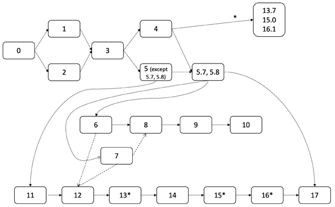

第13.7、15.0和16.1节依赖第4章，但它们所在各章的其余部分并不依赖。虚线表示建议遵循的依赖关系：先学第7章再学第8章和第12章，以及先学第6章再学第12章，都会有益，但并非绝对必要。Sections 13.7, 15.0, and 16.1 depend on Chapter 4, but the rest of their enclosing chapters do not. The dotted lines show recommended dependencies—it would be beneficial, but not absolutely required, to study Chapter 7 before Chapters 8 and 12, and likewise to study Chapter 6 before Chapter 12.

## Dafny语言Dafny

本书中的所有规约、程序和程序证明都使用Dafny编程语言，并且都可以在Dafny验证系统中检查。大体而言，Dafny语言的构造支持四类活动。All specifications, programs, and program proofs in the book use the Dafny programming language and can be checked in the Dafny verification system. Broadly speaking, the constructs of the Dafny language support four kinds of activities.

- 其中有用于命令式编程的构造，例如赋值语句、循环、数组和动态分配的对象。其中较简单的构造，是许多经典程序证明论述的基本内容。There are constructs for imperative programming, such as assignment statements, loops, arrays, and dynamically allocated objects. The simpler of these are the bread and butter of many classic treatments of program proofs.
- 其中有用于函数式编程的构造，例如递归函数和代数数据类型。在Dafny中，它们的行为与数学中的行为相同；例如，函数是确定性的，不能改变程序状态。There are constructs for functional programming, such as recursive functions and algebraic datatypes. In Dafny, these behave like in mathematics; for example, functions are deterministic and cannot change the program state.
- 其中有用于编写规约的构造，例如前置条件、循环不变式和终止性度量。这些构造融入语言的方式，受到了先驱性语言Eiffel以及Java建模语言（JML）的影响。规约可以使用任何函数式语言特性，因此表达力相当强。There are constructs for writing specifications, such as preconditions, loop invariants, and termination metrics. The way these are integrated into the language has been influenced by the pioneering Eiffel language and the Java Modeling Language (JML). Specifications can use any of the functional-language features, which makes them quite expressive.
- 最后，还有用于编写证明的构造，例如引理和证明演算。Lastly, there are constructs for proof authoring, such as lemmas and proof calculations.

这些不同的特性相互融合。例如，所有构造都使用相同的表达式语言；这些表达式包括链式表达式（如0 <= x < y < 100）、蕴含（==>）、量化（**forall**、**exists**）和集合（如{2, 3, 5}），它们常见于规约和数学，但也可以在程序中使用；方法、函数和证明以相同的方式把值绑定到局部变量；在方法中，**if**语句划分控制流，在引理中，它则划分证明义务；变量可以标记为**ghost**，使之适用于抽象，但除此之外，其行为与普通的编译变量一样；而归纳只需通过递归调用引理来实现，其终止性的规约和检查方式与方法和函数相同。These various features blend together. For example, all the constructs use the same expression language; these expressions include chaining expressions (like 0 <= x < y < 100), implication (==>), quantifications (**forall**, **exists**), and sets (like {2, 3, 5}), which are often found in specifications and math, but can also be used in programs; methods, functions, and proofs bind values to local variables in the same way; in a method, an **if** statement divides up control flow, and in a lemma, it divides up proof obligations; variables can be marked as **ghost**, which makes them suitable for abstraction, but otherwise behave as ordinary compiled variables; and induction is achieved simply by calling a lemma recursively, where termination is specified and checked in the same way as for methods and functions.

Dafny语言不仅功能多样，用途也很广泛。Dafny开发工具安装迅速，可用于Windows、MacOS和Linux。验证器会在VS Code集成开发环境中自动运行。Dafny程序可编译为多个语言平台上的可执行代码，包括.NET、Java、JavaScript和Go。工具集本身以开源形式发布，地址为：Not only is the Dafny language versatile, but so are its uses. The Dafny development tools are quick to install and are available on Windows, MacOS, and Linux. The verifier runs automatically in the VS Code integrated development environment. Dafny programs compile to executable code for several language platforms, including .NET, Java, JavaScript, and Go. The toolset itself is available as open source at

github.com/dafny-lang/dafny

在本书问世之前，Dafny就已经用于教学十余年。它还被用于若干令人瞩目的研究项目（例如微软研究院、VMware研究院、ConsenSys研发部门、卡内基梅隆大学、密歇根大学和麻省理工学院的项目），目前也已用于工业界（例如亚马逊云科技）。Even before this book, Dafny has been used in teaching for over a decade. It has also been used in several impressive research projects (for example, at Microsoft Research, VMware Research, ConsenSys R&D, CMU, U. Michigan, and MIT) and is currently in industrial use (for example, at Amazon Web Services).

## 在线信息Online Information

有关本书的一些补充信息可在线获取，地址为：Some additional information about this book is available online at

www.program-proofs.com

## 致谢Acknowledgments

本书能够完成，有许多人值得我感谢。I have many to thank for helping make this book possible.

我衷心感谢Rajeev Joshi、Rosemary Monahan、Bryan Parno、Cesare Tinelli，尤其是Graeme Smith，他们曾将本书早期草稿用于各自的大学课程教学。本书从他们及其学生的反馈中获益良多。I extend my deep gratitude to Rajeev Joshi, Rosemary Monahan, Bryan Parno, Cesare Tinelli, and especially Graeme Smith, who used earlier drafts of this book in teaching their university courses. The book has greatly benefited from their feedback, and from feedback of their students.

Rajeev Joshi、Yannick Moy、Jean-Christophe Filliâtre、Peter Müller和Ran Ettinger提供的详尽意见远远超出了应尽之责，实在大有帮助！我还收到了Nada Amin、Nathan Chong、David Cok、Josh Cowper、Mikaël Mayer、Gaurav Parthasarathy和Robin Salkeld提出的宝贵反馈。The detailed comments from Rajeev Joshi, Yannick Moy, Jean-Christophe Filliâtre, Peter Müller, and Ran Ettinger were much beyond the call of duty and were really helpful! I've also received good feedback from Nada Amin, Nathan Chong, David Cok, Josh Cowper, Mikaël Mayer, Gaurav Parthasarathy, and Robin Salkeld.

我感谢我所在的亚马逊云科技自动推理团队中的Byron Cook和Reto Kramer给予的鼓励。I'm grateful for the encouragement of Byron Cook and Reto Kramer in the Automated Reasoning Group where I work at Amazon Web Services.

以“程序证明”一词统称本书所讨论的这类科学与工程，是Nik Swamy的建议。The term “program proofs” as a rubric for the kind of science and engineering that this book is about was suggested by Nik Swamy.

我使用Madoko系统撰写和排版本书，感谢Daan Leijen创造Madoko，并帮助我进行定制。To write and typeset this book, I used the Madoko system, and I thank Daan Leijen for creating Madoko and for helping me with customizations.

特别感谢Kaleb，他为各章绘制了欢快的插图。A big shout-out to Kaleb, who drew the cheerful chapter illustrations.

最后，谢谢你，Gwen，感谢你充满爱意的支持，也感谢在我写作期间，你陪我在咖啡馆度过的无数个周末。Lastly, thank you, Gwen, for your loving support and the countless weekends we spent at coffee shops while I was writing.

谢谢大家！Thank you all!

K.R.M.L.

# 教师须知Notes for Teachers

一本书的内容选择和编排顺序，需要经过深思熟虑。在这里，我会更详细地说明各章的目的和编排动机。如果你是学习者，只想开始阅读本书，请直接跳到第0章。如果你是教师，想要规划课程大纲，这部分内容就是为你准备的。Much thought goes into the selection and order of material in a book. Here, I describe the purpose of and motivation for chapters in greater detail. If you're a learner and just want to get started with the book, skip ahead to Chapter 0. If you're a teacher and want to plan a course outline, this is for you.

## 第0部分Part 0

Dafny提供了相当高的自动化程度。因此，对于第13章中的循环和数组程序，大多只需给出必要的前置条件、后置条件和循环不变式，而不必费心处理证明细节。实践中，一旦离开那些较简单的程序，你总会遇到工具的自动化能力不够用的情况。程序证明的实践者需要知道如何应对这些情况，而第0部分旨在提供必要的基础。Dafny provides a considerable amount of automation. This allows you to write the loop and array programs in Chapter 13 mostly by just supplying the necessary pre- and postconditions and loop invariants, without the need to pain yourself with the details of the proofs. In practice, when you leave those simpler programs, you will always encounter situations where a tool's automation runs out. A program-proof practitioner needs to know how to deal with those situations, and Part 0 is aimed at providing the necessary foundations.

## 第0章Chapter 0

第0章为全书作铺垫，并说明如何安装Dafny集成开发环境（IDE）。Chapter 0 sets the stage for the book and gives instructions for how to install the Dafny integrated development environment (IDE).

## 第1章和第2章Chapters 1 and 2

第1章介绍方法、函数等编程概念，以及前置条件、后置条件等基本规约概念。Chapter 1 introduces some programming concepts like methods and functions, as well as fundamental specification concepts like pre- and postconditions.

如果你想从形式化的程序语义基础入手，那么（复习附录B后）第2章正适合你。如果你精于理解和处理形式化等式，那么你理想中的第2章或许只有一页，上面全是定义。大多数初学者还不能仅凭等式就获得启发，因此我在第2章中更循序渐进地介绍内容，并借助流程图等辅助方式。这些图呼应了Floyd的开创性工作；我还采用了Hoare以三元组解释程序行为的方式，以及Dijkstra在给定三元组另外两个分量时计算其第一个或最后一个分量的方式。If you want to start with the formal program-semantics underpinnings, then Chapter 2 (after reviewing Appendix B) is your friend. If you're a pro at understanding and dealing with formal equations, then your dream version of Chapter 2 would be a single page with just definitions. Most new learners are not equipped to be illuminated by equations alone, so I present the material in Chapter 2 more gradually and using aids like flow diagrams. The diagrams echo Floyd's seminal work, and I also incorporate Hoare's way of explaining program behavior using triples, as well as Dijkstra's way of computing the first or last component of such triples given the other two.

如果你对形式化等式兴趣不大，那么只需对第2章略加了解，就足以继续阅读本书其余部分，但有一个例外。在第2部分，尤其是第13章和第14章中，我常常通过对循环不变式和循环索引更新运用最弱前置条件，来计算必要的正确性条件。我将其称为“后向推理”。这些细节在第2章中逐步展开，我认为它们是理解命令式程序正确性的重要组成部分。If you're less interested in formal equations, then getting just a taste of Chapter 2 is enough for the rest of the book, with one exception. In Part 2, especially in Chapters 13 and 14, I often calculate necessary correctness conditions by applying weakest preconditions to a loop invariant and a loop-index update. I refer to this as “working backward”. Those details are built up in Chapter 2 and I think that forms an important part of understanding the correctness of imperative programs.

因为我希望读者尽可能“像程序员一样思考”，所以在第2章之前，先以更轻松、更非形式化的视角，说明如何推理程序各位置上的已知信息。对于擅长编程、但不太习惯数学公式的学习者，第1章可能是学习第2章的良好准备。这是我推荐的顺序，不过也有人使用本书时跳过第1章，直接学习第2章；或者先学习更形式化的第2章，再把第1章当作某些Dafny记法的初步指南。Because I want readers to be able to “think as a programmer” as much as possible, I have preceded Chapter 2 with a lighter, more informal view of what it means to reason about what is known at various program points. A learner who feels comfortable writing programs but less comfortable with math formulas may find Chapter 1 to be a good preparation for Chapter 2. That's what I recommend, but this book has also been used by skipping Chapter 1 and going straight to Chapter 2, or by starting with the more formal Chapter 2 and then using Chapter 1 as a first guide to some Dafny notation.

## 第3章Chapters 3

第3章讨论终止性，围绕良基序的概念及其对递归调用的应用展开（循环的终止性在介绍循环推理的第11章中讨论）。把终止性一章安排在全书如此靠前的位置，也许显得奇怪。确实，许多Dafny程序都能在完全不受终止性问题干扰的情况下编写出来，因为Dafny会全自动处理很大一部分终止性问题。然而，我发现，当用户第一次碰到需要人工介入终止性证明的程序时，那种意外感，以及为理解下一步该怎么办而必须补学的知识，会让人绕很大一个弯。因此，我发现，在其他问题还没有变得复杂之前，及早讲解终止性会更容易。此外，做一些终止性证明，也为学习者提供了练习人与验证器交互的好机会。Discussing termination, Chapter 3 centers around the concept of a well-founded order and how that applies to recursive calls (termination for loops is covered in Chapter 11, which introduces reasoning about loops). It may seem odd to place a chapter on termination so early in a book. Indeed, many programs can be written in Dafny without any distraction from concerns about termination. This is because Dafny handles a large proportion of termination concerns completely automatically. What I have found, however, is that the day when a user first encounters a program that requires manual intervention in a termination proof, the surprise and additional learning necessary to understand what to do next require a large detour. Therefore, I have found termination to be an easier topic to cover early, before other concerns have become complicated. Besides, doing some termination proofs provides a learner with good opportunities to practice human-and-verifier interactions.

及早讲解终止性还有一个重要原因。不理解终止性，就很难解释数学归纳法，而且会使其显得极其神秘。第5章、整个第1部分以及第12章都大量依赖归纳证明，因此在进入这些章节之前充分理解终止性，会很有帮助。There is one more important reason to cover termination early. Without understanding termination, it is diﬃcult and highly mysterious to explain mathematical induction. Chapter 5, all of Part 1, and Chapter 12 rely heavily on inductive proofs, so coming into those chapters with a good understanding of termination is helpful.

我确实想指出，我看待归纳的方式与许多数学教材不同。许多教材对归纳的基本情形、归纳假设、归纳步骤的格式要求非常严格。这些格式通常称为*归纳模式*。在高中介绍归纳法时，这种严格格式提供了更好的“护栏”；而在逻辑或类型论中，当人们想要正式*论证*归纳法为何有效时，归纳模式也发挥着重要作用。但按照我的介绍方式，数学归纳法就是递归调用引理。向程序员教授递归时，不会规定递归调用必须遵循某种严格的语法格式，也不会要求在递归方法的方法体前，先声明某种“递归模式”。相反，程序员习惯于在需要针对规模更小的问题再次获得该方法的行为时，进行递归（或相互递归）调用。而这些递归调用*正确性*的一个关键要素，就是它们的终止性。这就是我在本书中教授归纳的方法：你可以自由地递归调用任何引理，但调用时要确保该递归调用终止。换句话说，终止性并不是内置于某种递归模式中的，而是你应当为任何调用证明的一项良好规范。I do want to point out that I think of induction in a different way than many math texts. Many treatments of induction are very strict about the format of base case/induction hypothesis/induction step. These are often known as *induction schemas*. The strict format gives better “side bumpers” for high school introductions to induction, and induction schemas play an important role in logic or type theory where one wants to give formal *justifications* of why induction works. But the way I present it, mathematical induction is just about calling lemmas recursively. When recursion is taught to programmers, you don't talk about some strict syntactic format for how recursive calls must be done, or some pre-declared “recursion schema” that precedes the body of a recursive method. No, programmers are used to making a recursive (or mutually recursive) call whenever they have a need to obtain the method's behavior again on a smaller problem size. Now, a key ingredient to the *correctness* of such recursive calls is their termination. That is how I teach induction in this book—feel free to call any lemma recursively, but when you do, make sure the recursive call terminates. In other words, termination is not built into some kind of recursion schema, but is instead a good-hygiene thing that you prove of any call.

本书中的归纳证明，大部分仍然遵循简单的归纳模式，采用久经考验的惯用语法格式。因此，如果你以前只以这种方式使用过归纳法，也完全不用担心。（不过，第5.6节有个例子，突出了两者的差别。）For the most part, inductive proofs in this book do follow simple induction schemas using tried-and-true idiomatic syntactic formats. So, don't get all worried if that's the only way you've used induction before. (But see Section 5.6 for an example that highlights the difference.)

总之，这就是为何早在第3章就讨论终止性。Anyhow, that's why termination is covered already in Chapter 3.

## 第4章Chapter 4

第4章介绍代数数据类型。本章很简单，有函数式编程背景的读者会熟悉其中的内容。把它安排在这里，是因为代数数据类型非常适合用于教授证明，而证明正是随后各章的主题。整个第1部分大量使用数据类型，第2部分的某些节也会用到。Chapter 4 introduces algebraic datatypes. It is a simple chapter and its material will be familiar to those with a functional-programming background. This chapter is placed here because algebraic datatypes are great for teaching proofs, which is the subject of the subsequent chapters. Datatypes are used heavily throughout Part 1, and they are also used in some sections of Part 2.

## 第5章Chapter 5

手工编写证明的能力，对任何非平凡的程序开发都至关重要。第5章的作用就是教授如何做到这一点。重点在于定理和证明的表述，因此我为定理选择了尽可能熟悉的主题：算术和前一章介绍的代数数据类型。我建议先学第4章再学第5章，但如果同时跳过第5.7和5.8节，也可以跳过第4章。Being able to write manual proofs is essential to any nontrivial program development. The role of Chapter 5 is to teach how this is done. The focus is on the formulation of theorems and proofs, so I have chosen the subject of the theorems to be as familiar as possible—arithmetic and the algebraic datatypes introduced in the preceding chapter. I recommend Chapter 4 before Chapter 5, but it is possible to skip Chapter 4 if you also skip Sections 5.7 and 5.8.

学完第5章后，如果还想多做证明练习，我推荐第6章和第7章，两章的学习顺序不限。If you want more proof practice even after Chapter 5, then I recommend Chapters 6 and 7, in either order.

在数学中，证明有两种作用。一种是向其他数学家传达证明；另一种是在发展定理的过程中充当思考工具。对于程序，证明也有相同的两种作用。当证明由机器检查时，我所说的交流发生在用户与自动验证器之间。因此，必须通过与验证器交互来练习证明，就像掌握一门外语不能只靠读书一样：你需要把它当作交流方式来练习使用。In mathematics, there are two roles of a proof. One role is to communicate a proof to other mathematicians. The other is as a thinking tool during the development of a theorem. For programs, proofs have the same two roles. When a proof is machine checked, the communication I mentioned is between the user and the automated verifier. It is therefore crucial that proofs be practiced interactively with the verifier, just as reaching fluency in a foreign language cannot be gained just by reading books—you need to practice using it as a way of communication.

所以，不要满足于只是*阅读*第5章。请亲自重做证明的各个步骤，切身体会与验证器的交互。也要做习题，因为这时下一步该做什么的“答案”不会就摆在眼前的书页上。我相信，学习者此时必定迫切地想深入编写程序，但学会如何编写证明、如何与自动验证器沟通，绝对值得投入这些时间。So, don't be satisfied by just *reading* Chapter 5. Redo the steps of the proofs yourself so you get to experience the interaction with the verifier firsthand. Also, do exercises, where the “answer” to what to do next is not right in front of you on the page. As eager as I'm sure the learner will be at this point to dig into programs, learning how to write proofs and communicate with the automated verifier will be well worth the time so invested.

## 第1部分Part 1

第1部分在函数式程序的背景下教授规约与证明。对于程序证明，这种背景有两个主要优点。其一是数据结构不可变，因此无须跟踪程序状态的变化。另一个优点是，数据和操作往往以递归方式定义，这为组织证明提供了一致而自然的方式。即便你编写的大多数程序是命令式的，你也会在规约中使用函数式程序片段。如果编程语言同时提供命令式和函数式构造（如Dafny），你会发现，在命令式程序中那些实际上不可变的部分，函数式特性有许多很好的用途。Part 1 teaches specifications and proofs in the setting of functional programs. With regard to program proofs, this setting has two main advantages. One is that data structures are immutable, so there is no need to keep track of changes to the program state. The other advantage is that data and operations tend to be defined recursively, which gives a consistent and natural way to structure proofs. Even if most of the programs you write are imperative, you will use functional program fragments in specifications. And if the programming language offers both imperative and functional constructs (like Dafny does), you will find many good uses of functional features in those parts of your imperative programs that are in fact immutable.

## 第6章、第7章和第8章Chapters 6, 7, and 8

第6章介绍为归纳定义的数据结构，尤其是列表，编写规约和进行推理的基本方法。第7章接着介绍一元数的归纳表示。虽然一元数本身并不特别有趣，却提供了充分练习证明技巧的机会。第8章为两个排序算法编写规约并进行验证。Chapter 6 introduces the basic ways to specify and reason about inductively defined data structures, and in particular lists. Chapter 7 follows that up with an inductive representation of unary numbers. Although not so interesting by themselves, unary numbers give ample opportunity to practice proof skills. Chapter 8 specifies and verifies two algorithms, both for sorting.

## 第9章和第10章Chapters 9 and 10

第9章和第10章考察较大程序的结构，关注抽象和信息隐藏。这些概念是良好计算机科学的核心，对程序证明也至关重要。与向客户暴露过多实现细节的模块相比，提供高层次抽象的模块，往往既更容易使用，也更容易验证。Chapters 9 and 10 look at the structure of larger programs, paying attention to abstraction and information hiding. These concepts are at the core of good computer science and also play a crucial role for program proofs. A module that provides a high level of abstraction is often easier to both use and verify than a module that reveals too many implementation details to its clients.

模块化、抽象和信息隐藏同样适用于命令式程序，不过本书先在第1部分讨论这些主题。尽管如此，第2部分仍然可以不先读第1部分就直接阅读。Modularity, abstraction, and information hiding apply equally well to imperative programs, but the book first covers these topics in Part 1. Still, Part 2 can be read without first reading Part 1.

第9章介绍将代码组织成模块的一些具体机制。其中涉及许多细小的设计决定：哪些内容向模块外部公开，哪些内容隐藏在模块内部。Chapter 9 introduces some mechanics of structuring code into modules. It touches on many small design decisions about what to reveal outside the module and what to hide inside the module.

第10章介绍计算机科学的另一块基石：不变式。这里的不变式描述不可变数据结构的性质；第2部分的不变式则描述循环迭代之前的状态（第11章），以及可变数据结构的稳定状态（第16章）。Chapter 10 introduces another cornerstone of computer science: invariants. Here, the invariants talk about the properties of immutable data structures, and in Part 2 the invariants talk about the state before loop iterations (Chapter 11) and the steady state of mutable data structures (Chapter 16).

第10章和第16章都将数据结构不变式表达在一个按惯例命名为Valid()的谓词中。这使函数式和命令式环境的处理更统一，减少了理解不变式所需的概念，并始终明确说明*哪些*性质在*何处*成立。显式Valid()谓词的缺点是可能使规约冗长。多种语言（包括Dafny）提供*谓词子类型*（又称*子集类型*、*精化类型*或*依赖类型*），实际上将Valid()谓词纳入类型。如果第1部分再多两章，我也会介绍它们；但在两者之间取舍时，我决定将类型与其他不变式分开处理。Chapters 10 and 16 both capture the data-structure invariants in a predicate by convention named Valid(). This gives a more uniform treatment of the functional and imperative settings, reduces the number of concepts needed to understand invariants, and always makes it clear *what* properties hold and *where* they hold. The downside of the explicit Valid() predicates is that they can make specifications verbose. Various languages (including Dafny) provide *predicate subtypes* (aka *subset types*, *refinement types*, or *dependent types*) that in effect incorporate the Valid() predicate into a type. With two more chapters in Part 1, I would have covered them, too, but in choosing between them, I decided on keeping types and other invariants separate.

## 第2部分Part 2

第2部分介绍对命令式程序进行推理的方法。虽然第1部分不是第2部分的先修内容，但命令式程序确实会使用函数和模块来组织代码、编写模块化规约。第2部分会按需介绍这些内容，更完整的论述则参见第1部分。如前所述，如果你想学好命令式程序的证明，而不只是快速浏览第11章，我强烈建议先学习第0部分中的终止性和证明概念。Part 2 introduces ways to reason about imperative programs. While Part 1 is not a prerequisite of Part 2, imperative programs do use functions and modules to organize code and write modular specifications. Part 2 speaks about these as needed, but refers to Part 1 for a fuller treatment. As I've mentioned before, if you want to learn to do proofs well for imperative programs (beyond a quick tour of Chapter 11), I strongly recommend first learning the concepts of termination and proofs from Part 0.

## 第11章Chapter 11

循环是命令式编程中最显著的构造之一。第11章的主题，就是利用循环不变式对循环进行推理。大多数初学者都会在循环不变式上遇到困难。从教学角度，我有两条关于循环的建议，本书都体现了这两点。One of the most conspicuous programming constructs in imperative programming is the loop. Reasoning about loops using loop invariants is the subject of Chapter 11. Most beginners struggle with loop invariants. From a teaching perspective, I have two recommendations about loops, both of which are reflected in the book.

第一条建议是，把循环不变式视为循环的规约，而不是事后为了说明循环体做了什么才补上的东西。实现这一点的一种方法，是把循环体隐藏起来。现场演示时，可以利用IDE的大纲功能折叠循环体，达到这种效果。在Dafny中，你甚至可以完全省略循环体！例如，Dafny验证器会接受以下程序，并证明它正确：The first recommendation is to treat loop invariants as specifications for loops, rather than as an afterthought that seeks to explain what the loop body does. One way to do this is to hide the loop body from view. In a live demonstration, you can get this effect by collapsing the loop body using the IDE's outlining features. In Dafny, you can also do this by omitting the body of a loop altogether! For example, the Dafny verifier will accept and prove correct the program

**method** BodylessLoop() {

**var** s, n := 0, 0;

**while** n < 100

**invariant** 0 <= n <= 100 && s == 4 * n

**assert** s + n == 500;

}

即使循环体被省略了，也是如此。需要传达的要点是：对循环使用方式的推理只依据不变式，*不*窥视循环体；而对循环体正确性的推理，则不考虑循环在何处使用。也就是说，循环不变式就像使用循环的上下文与循环实现之间的一份契约。这与依据方法的规约、而不是实现来推理方法的思想相同（第1章对此作了说明）。然而，我发现，对循环来说，这一思想比对方法更难讲清楚；我猜是因为循环体“就在那里”，初学者无法抵抗查看循环体的诱惑。despite the fact that the body of the loop is omitted. The point that needs to come across is that one reasons about the use of the loop from the invariant alone, *without* peering into its body, and one reasons about the correctness of the body without considering where the loop is used. That is, the loop invariant is like a contract between the context that uses the loop and the implementation of the loop. This is the same idea as reasoning about methods in terms of their specifications, not their implementations (as explained in Chapter 1). Yet, I have found that this idea is harder to get across for loops than for methods, which I suspect is because the loop body is “right there” and it's impossible for beginners to resist the temptation to look at the loop body.

所以，学习循环不变式时，我建议尽可能把循环规约与循环体分开。（强调这一点的其他资料包括Hehner[61]和Morgan[93]。）So, when learning about loop invariants, my recommendation is to try, as much as possible, to separate the loop specification from its body. (Others sources that stress this include Hehner [61] and Morgan [93].)

我教授循环时的另一条建议，是避免使用**for**循环。熟悉循环不变式之后，**for**循环既方便又简洁。但在理解不变式之前，循环索引的更新（例如i := i + 1;）是隐式的这一点，会使人更难理解不变式究竟应该对循环索引的哪个值成立。此外，如果看不到循环体末尾的循环索引更新，就很难解释从循环不变式“后向推理”这一有用步骤。My other recommendation when teaching about loops is to avoid **for** loops. Once you're comfortable with loop invariants, **for** loops are convenient and concise. But before you understand invariants, the fact that the update of the loop index (e.g., i := i + 1;) is implicit makes it much harder to understand what value of the loop index the invariant is supposed to hold for. Also, the helpful step of “working backward” from the loop invariant becomes hard to explain if you cannot see the loop-index update at the end of the loop body.

所以，我建议教学时坚持使用更冗长的**while**循环（至少在学完第13章之前如此）。So, my recommendation is to stick with the more verbose **while** loops when teaching (at least until after Chapter 13).

## 第12章Chapter 12

第11章介绍循环和循环不变式之后，第12章介绍一个实践中很重要的主题：从递归定义的规约走向迭代定义的实现。我认为，许多要求手工证明的程序验证书籍都遗漏了这个主题。用纸笔工作时，你可以自由发明方便的记法，你“知道”它们表达什么，而无须完全形式化。例如，可以用下面的记法表示从*a*到*b*之间满足谓词*P*的整数个数：After the introduction of loops and loop invariants in Chapter 11, Chapter 12 introduces a practically important topic: going from recursively defined specifications to iteratively defined implementations. I think this topic was omitted from many of the program-verification books that expected proofs to be done by hand. When you do this work with paper and pen, you are free to invent convenient notations where you “know” what they say without having to be entirely formal about them. For example, you may notate the number of integers from *a* to *b* that satisfy a predicate *P* by

(*#i* :: *a* ≤ *i* < *b* ∧ *P* (*i*))

这种记法的妙处在于，它不涉及从哪一“端”移除元素。例如，如果用∥*P* (*a*)∥表示：*P* (*a*)成立时为1，否则为0，那么对于*a < b*，性质This notation is beautifully agnostic about which “end” you remove an element from. For example, if we write ∥*P* (*a*)∥ to denote 1 if *P* (*a*) holds and 0 otherwise, then, for *a < b*, the properties

(#*i* :: *a* ≤ *i* < *b* ∧ *P* (*i*)) = ∥*P* (*a*)∥ + (#*i* :: *a* + 1 ≤ *i* < *b* ∧ *P* (*i*))

和and

(#*i* :: *a* ≤ *i* < *b* ∧ *P* (*i*)) = (#*i* :: *a* ≤ *i* < *b* − 1 ∧ *P* (*i*)) + ∥*P* (*b* − 1)∥

同样显而易见。但如果#概括式是递归（归纳）定义的——这在计算机辅助验证系统中最为常见（除非#是内置的，例如参见[81]）——那么你就必须选择在范围*a ≤ i < b*的哪一端进行递归（归纳）。这会影响验证计算这些结果的循环时所需做的工作，因为循环也必须选择循环索引变化的方向（递增或递减）。我见过许多人（不只是初学者）在这一点上卡住，所以在第13章及以后讨论更有趣的算法之前，我专门用第12章来讨论这一主题。are equally obvious. But if the # comprehension is defined recursively (inductively), which is most likely in a computer-aided verification system (unless # is built in, see e.g. [81]), then you have to choose at which end of the range *a ≤ i < b* the recursion (induction) happens. This has an effect on what you have to do when verifying a loop for computing these things, since a loop also has to choose which direction (up or down) to evolve the loop index. I have seen many people (not just beginners) get stuck on this point, which is why I have devoted Chapter 12 to this topic, before doing more interesting algorithms in Chapter 13 and beyond.

## 第13章Chapter 13

1980年代不仅带来了许多好音乐，也带来了几本出色的程序证明书籍。Backhouse[12]、Cohen[29]、Dijkstra和Feijen[41]、Gries[55]、Hehner[61]、Kaldewaij[68]、Morgan[93]、Reynolds[113]以及Van de Snepscheut[122]的经典佳作，通常先讲一些布尔代数，再讲一些形式化程序语义（一般是Hoare三元组或最弱前置条件），最后讲一些可以称为“循环和数组程序”的应用实例。这些都是极好的教材。遗憾的是，1980年代没有带来足以在计算机上完成这些程序证明的CPU速度和工具。The 1980s brought not just a lot of good music but also several excellent books on program proofs. The classic gems by Backhouse [12], Cohen [29], Dijkstra and Feijen [41], Gries [55], Hehner [61], Kaldewaij [68], Morgan [93], Reynolds [113], and Van de Snepscheut [122] often covered some Boolean algebra, then some formal program semantics (typically Hoare triples or weakest preconditions), and finally some example applications of what you might call “loop and array programs”. These are wonderful textbooks. It's too bad the 1980s didn't bring the CPU speeds and tools needed to carry out these program proofs on a computer.

如果你熟悉这些经典书籍，那么阅读第13章会倍感亲切，其中讨论了几个有趣而富有启发性的算法，许多直接受到经典教材中例子的启发。如果仔细挑选第13章中的部分小节，也可以跳过第12章。不过，对于想学好程序证明的人，我认为第12章中的考量，至少与证明第13章中的算法一样具有启发性。If you're familiar with these classic books, you'll feel right at home with Chapter 13, which covers several fun and instructive algorithms—many of which have been directly inspired by examples in the classic textbooks. If you carefully pick a subset of the sections in Chapter 13, you could get away with skipping Chapter 12. However, for someone wanting to learn program proofs well, I think the considerations in Chapter 12 are at least as instructive as proving the algorithms in Chapter 13.

一门很好的程序证明入门课程，可以先讲解或复习附录B的布尔代数，再讲解第2章的部分程序语义，然后学习第11、12、13章的循环和数组程序。尽管这样不如从完整的第0部分开始，能够达到同样的深度和实践熟练程度，但它为学习者提供了一条更快的途径，去证明有趣的小程序的性质。A fine introductory course on program proofs would be to cover or review the Boolean algebra in Appendix B, then cover (some of) the program semantics in Chapter 2, followed by the loop and array programs in Chapters 11, 12, and 13. Although this wouldn't give the same depth and practical fluency as starting with all of Part 0, it gives the learner a quicker path to proving properties of small, interesting programs.

## 第14章和第15章Chapters 14 and 15

第15章继续讨论更多数组算法，但由于这些算法（与第13章的算法不同）会*修改*数组，我先在第14章介绍状态修改这一主题。它属于更一般地称作*框架限定*的内容。第14章对框架限定的介绍足够平缓，因此适合作为第15章的先修内容。Chapter 15 continues with more algorithms on arrays, but since those algorithms (unlike the ones in Chapter 13) *modify* the arrays, I first introduce the topic of state modifications in Chapter 14. This topic is part of what more generally is called *framing*. The Chapter 14 introduction of framing is gentle enough that it justifies being a prerequisite for Chapter 15.

我想，许多希望涵盖命令式程序证明全部基础知识的大学课程，会发现第15章很适合作为最后一章。I imagine that many university classes that want to cover all the basics of program proofs for imperative programs will find Chapter 15 to be a good chapter to end with.

## 第16章和第17章Chapters 16 and 17

本书最后两章介绍对动态分配的数据结构进行更困难的修改。一些来自C或Java类语言的程序员，可能急于攻克这些章节。这当然很好，但我觉得必须指出，许多编程任务同样可以用本书第1部分那样的不可变数据结构很好地完成。上一句中，我本可以说“必须提醒”而不是“必须指出”，但根据我的经验，对于主要使用的编程语言不支持此类类型的人，这一点并不总是显而易见。如果你的问题可以用数据类型而不是类来解决，那么你的证明工作就会更少、更愉快（例如，注意习题16.4中的类使用了数据类型List，而不是通过指针串接起来的命令式链表）。The final two chapters of the book introduce more diﬃcult mutations of dynamically allocated data structures. Some programmers who come from C- or Java-like languages may feel an urgent need to conquer these chapters. That's all good, but I feel compelled to point out that many programming tasks can be performed equally well using immutable data structures like those in Part 1 of the book. I might have said “compelled to issue the reminder that” in the previous sentence instead of “compelled to point out that”, but in my experience, this point is not always apparent to those whose primary programming language does not offer support for such types. If your problem can be solved with datatypes rather than with classes, then your proof effort will be both smaller and more pleasant (note, for example, that the class in Exercise 16.4 uses a datatype List rather than an imperative linked list stitched together via pointers).

第16章和第17章解释如何为可能随时间演变、在堆上分配的可变数据结构编写规约并进行验证。与第9章和第10章中为不可变数据结构编写规约相比，使这件事更困难的主要差别在于框架限定。从本质上说，框架限定就是跟踪（或者在某些情况下分离）可变数据结构所使用的全部对象。第14章已针对简单情形介绍过这一点，因此第16章和第17章新增的主要要素是抽象，即能够将框架规定为某个特定对象集合，而不必向客户透露这些对象的确切身份。Chapters 16 and 17 explain how to specify and verify mutable, heap-allocated data structures that may evolve over time. The main difference that makes this more difficult than specifying the immutable data structures of Chapters 9 and 10 is framing. Essentially, framing comes down to keeping track of (or, in some cases, separating) all the objects that are used as part of a mutable data structure. This was introduced for simple cases in Chapter 14, so the main ingredient that is added in Chapters 16 and 17 is abstraction, that is, the ability to specify a frame to be a particular set of objects without having to divulge the exact identities of those objects to clients.

有趣的是，语言中处理框架限定和抽象所需的设施，仅仅是**modifies**/**reads**子句、集合和幽灵变量。因此，最后两章很好地建立在本书先前内容的基础之上。有些语言和验证器转而提供限制对象引用使用的方法。这可以简化某些规约模式，但需要解释所施加的限制（例如Spec#[13]或Rust[115]式的对象所有权系统），或更复杂的底层逻辑（例如分离逻辑[64]或隐式动态框架[98]）。问题和关注点是相同的，所以从使用本书规约中学到的知识，也能迁移到其他形式化体系。It's interesting that the only facilities needed in a language to handle framing and abstraction are **modifies**/**reads** clauses, sets, and ghost variables. Hence, these two last chapters build nicely on previous material in the book. Some languages and verifiers instead provide ways to restrict the use of object references. This can streamline some patterns of specifications, but requires explaining the restrictions imposed (like systems of object ownership à la Spec# [13] or Rust [115]) or the more complicated underlying logics (like separation logic [64] or implicit dynamic frames [98]). The issues and concerns are the same, so what is learnt from using the specifications in this book carries over to other formalisms.

## 关于省略的一些内容On some material omitted

有些程序比另一些程序更难通过机械化验证器的检查。我尽量避免这类复杂情况。例如，本书只有限度地使用乘法，因为多个变量相乘通常是自动化能力较弱的领域。如果你自行设计习题，我建议不要大量使用乘法（而且务必先亲自试做这些习题）。Some kinds of programs are trickier to get past a mechanical verifier than others. I've tried to avoid such complications when possible. For example, the book uses only a limited amount of multiplication, because multiplication of several variables is an area where automation is typically weaker. If you design your own exercises, then I suggest not going rampant with the use of multiplication (and make sure you first try the exercises yourself).

其他需要一些技巧的表达式包括量词和概括式。本书有很多量词，但我尽量避开嵌套或其他复杂的量词。（第13章以前唯一使用量词的程序，是第10章中的IsMin谓词。）量词很重要，但在学生充分理解程序证明并熟练掌握与验证器交互之前，就让他们面对驾驭量词的各种手段，既不公平，也无必要。Other expressions that require some finesse are quantifiers and comprehensions. There are plenty of quantifiers in the book, but I've tried to stay clear of nested or otherwise complicated quantifiers. (And the only program that uses quantifiers before Chapter 13 is the IsMin predicate in Chapter 10.) Quantifiers are important, but it's both unfair and unnecessary to subject students to the ways of taming quantifiers until after they acquire a good understanding of program proofs and a fluency in interacting with the verifier.

我没能避开的一个棘手领域，是集合类类型（尤其是多重集和序列）的*外延性*。在第10.2.4节和第13.4节中，我会稍作岔开，解释所需的内容。One tricky area that I was not able to avoid is that of *extensionality* for collection types (in particular, multisets and sequences). In Sections 10.2.4 and 13.4, I include some detours to explain what is needed.

# 第0章 引言Chapter 0 Introduction

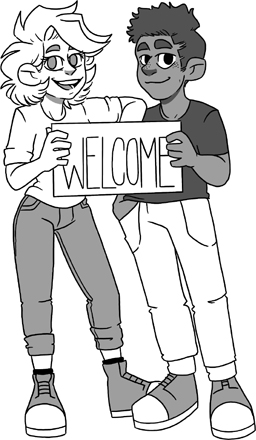

对我们许多人来说，编程始于一些简单脚本：在终端上打印消息，在屏幕上显示各种颜色的矩形，甚至在朋友的移动设备之间发送聊天消息。编写或修改这样的程序，就是添加几行代码，然后运行程序，看看改动产生了什么效果。当我们终于看到程序打印出“你好，Rustan！”，显示出水绿色*和*品红色的矩形，或者在聊天消息含有特定关键词时自动插入表情符号，就会因程序按照我们的意愿运行而感到成就。程序*能用了*！For many of us, programming started with some simple scripts that print messages on a terminal, display rectangles of various colors on the screen, or maybe even send chat messages between friends on mobile devices. The process of writing or modifying such a program is to add a couple of lines of code and then run the program to see what effect your change had. When we finally see the program print “Hello, Rustan!”, show rectangles that are aqua *and* magenta, or automatically insert emojis when chat messages contain certain keywords, then we feel a sense of accomplishment that our program behaves like we want. The program *works*!

并非所有程序都是这样。通常，我们不能只运行一次程序，就断定它始终能正常工作，也就是断定程序*正确*。事实上，我们可能运行了许多次程序，感觉它是正确的，但随后有人（也许是我们以软件为支撑的服务型企业的客户）找到了某种使用方式，使程序表现出我们未曾预期的行为。程序崩溃了。程序破坏了客户数据。更糟的是，程序使未经授权的人得以访问个人信息。我们希望知道自己的程序没有这些问题。但怎样才能判断程序是否正确呢？甚至，对于这样的程序，正确究竟意味着什么？Not all programs are like that. Typically, we can't just run a program once and determine that it always works—that the program is *correct*. In fact, we may run the program many times and get the feeling it is correct, but then someone (maybe a customer of our service-oriented software-powered business) finds a way to use the program that causes it to behave in a way we did not intend. The program crashes. The program corrupts customer data. Worse, the program enables unauthorized access to personal information. We'd like to know our programs do not suffer from such problems. But how can we tell if a program is correct? And what does it even mean for such a program to be correct?

对程序行为进行推理，就是本书的主题。最好在至少学习了一学期，甚至两学期的编程之后，再接触这个主题。这意味着你已经习惯了基本编程构造，写过一些曾让你费力钻研的程序，也亲自尝试过判断程序是否正确、如何测试和调试它们，以及如何反复尝试将其改正。Reasoning about the behavior of programs is the subject of this book. The subject is best approached after you have done at least a semester of programming, maybe even two. This means you're accustomed to basic programming constructs. You've written some programs that you've struggled with. You've tried your own hand at determining if your programs are correct, how to test and debug them, and how to try—repeatedly—to correct them.

本书教你如何思考程序，以及如何*证明*它们正确，也就是如何构造精确的论证，表明程序按预期运行。这些严密的论证也有助于磨炼思维，使你更容易理解如何编写*确实*正确的程序；毕竟，只有*确实*正确的程序，才可能被*证明*正确。证明程序正确性的过程，往往会发现缺陷（错误、瑕疵、遗漏、笔误、思维疏漏，随你怎么称呼），而修复这些缺陷，也是通往正确性之路的一部分。This book teaches you how to think about programs and how to *prove* them correct, that is, how to construct precise arguments that show the programs behave as intended. Such rigorous arguments also help sharpen your thinking, so that you more readily understand how to write programs that *are* correct—after all, the only programs that you can *prove* to be correct are those that *are* correct. The process of proving a program's correctness often discovers bugs (errors, defects, omissions, typos, think-o's, call them what you may), and fixing the bugs is part of the road to correctness.

对程序进行精确推理的技术，统称为*形式化方法*。这个名称意味着运用精确的数学、逻辑和形式化证明。确实，贯穿本书，我都会使用严格的证明和详尽的逻辑论证；事实上，其详细程度足以让计算机机械地检查这些论证。这个形式化过程中涉及的基本概念（例如*前置条件*或*不变式*），在非形式化描述程序行为时也同样有用。形式化的机器辅助过程，有助于确保你不会遗忘或遗漏任何细节，并且在程序发生修改时，可以自动重新应用。Techniques that reason precisely about programs fall under the rubric of *formal methods*. This name implies the use of precise mathematics, logic, and formal proofs. Indeed, throughout the book, I will make use of rigorous proofs and detailed logical justifications—in fact, so detailed that the justifications can be mechanically checked by a computer. The basic concepts that go into this formal process (for instance, the concept of a *precondition* or *invariant*) are useful also when describing a program's behavior informally. The formal, machine-assisted process helps you make sure you don't forget or miss any details, and it can be reapplied automatically when a program undergoes changes.

## 0.0. 预备知识0.0. Prerequisites

在本书教授程序推理的过程中，我将介绍规约、抽象、引理以及大量证明。我不假定你事先了解这些主题。如果你在高中做过归纳证明，并且还记得它是怎么回事，那可能会有所帮助，但并非必需。（事实上，如果你对归纳等主题非常熟悉，你可能会发现，我教授和思考这些主题的方式，与某些常见论述有所不同。我把这归因于：我是一名程序员，而不是逻辑学家。）As part of teaching you how to reason about programs in this book, I will teach you some things about specifications, abstraction, lemmas, and (a lot of) proofs. I do not assume you have any prior knowledge of these topics. If you did some proofs by induction in high school and remember what that was all about, that may be a plus, but it's not necessary. (In fact, if you have a lot of familiarity with topics like induction, you may find that I teach them and think about them in a way that differs from some common accounts. I attribute this to the fact that I'm a programmer, not a logician.)

我确实假定你熟悉程序编写。具体而言，我假定你实际掌握了变量、绑定与可变赋值、**if**语句、循环和递归。我假定你理解：程序执行是沿着程序语句前进的一条轨迹（控制流），而程序状态由程序变量的值（程序数据）构成。What I do assume is that you are familiar with writing programs. Specifically, I assume you have a working knowledge of variables, bindings and mutable assignments, **if** statements, loops, and recursion. I assume you understand the idea that a program execution is a trace through the program's statements (the control flow) and that the state of a program consists of the values of the program's variables (the program data).

编程时不可避免会学到的那部分逻辑，是布尔值（**false**和**true**）以及对这些值的常用运算。我假定你见过“A与B”“A或B”以及“非A”这样的表达式。在逻辑中，它们通常分别记作The part of logic that one unavoidably learns when writing programs is booleans (**false** and **true**) and the common operations on these values. I assume you've encountered expressions like “A and B”, “A or B”, and “not A”. In logic, these are often notated, respectively, as

*A* ∧ *B* *A* ∨ *B* ¬*A*

而在编程记法中（本书也如此），它们更常写作whereas in programming notation (and in this book), they are more often written as

A && B A || B !A

逻辑“与”也称为*合取*，所以我们把&&的操作数称为*合取项*。类似地，逻辑“或”称为*析取*，所以我们把||的操作数称为*析取项*。否定运算符的结合力强于“与”和“或”，因此!A && B与(!A) && B相同；而如果你想表示A和B至多有一个成立，就必须保留!(A && B)中的括号。Logical “and” is also called *conjunction*, so we refer to the operands of && as *conjuncts*. Similarly, logical “or” is called *disjunction*, so we refer to the operands of || as *disjuncts*. The negation operator binds stronger than “and” and “or”, so !A && B is the same as (!A) && B, and you have to leave the parentheses in !(A && B) if you intend to express that at most one of A and B holds.

规约中经常使用逻辑表达式“A蕴含B”。这个表达式记作*A ⇒ B*或A ==> B，意思是“如果A为**true**，那么B也为真”。它可以用其他运算符写成!A || B，但箭头往往能使我们更直观地理解规约中蕴含的用法。例如，假设要写下“如果我在咖啡馆，就喝浓缩咖啡”和“如果我在健身房，就喝水”。可以清楚地将它们表述为In specifications, the logic expression “A implies B” is often used. Notated as *A ⇒ B* or A ==> B, this expression says that “if A is **true**, then so is B”. It can be written in terms of the other operators as !A || B, but the arrow many times improves the intuitive understanding of how we use implication in specifications. For example, suppose we want to write down “if I'm at a coffee shop, then I drink espresso” and “if I'm at the gym, then I drink water”. These are nicely formulated as

(AtCoffeeShop ==> DrinkEspresso) && (AtGym ==> DrinkWater)

运算符==>的结合力弱于&&和||；==>占3个字符，其他运算符只占2个字符，这也提示了这种关系。The operator ==> binds weaker than && and ||, as is suggested by the fact that ==> is 3 characters wide, whereas the others are only 2 characters wide.

## 习题0.0。Exercise 0.0.

用!A || B形式，而不是A ==> B形式，写出这个关于饮品的蕴含式。务必在适当位置使用括号。你觉得哪种表述更容易理解？Write this drink implication using the form !A || B instead of the form A ==> B. Be sure to use parentheses in the right places. Which formulation do you find easier to understand?

蕴含的箭头记法也暗示了A与B之间的一个序关系。如果A ==> B这个条件始终成立，那么我们就说A比B*强*，而B比A*弱*。例如，AtCoffeeShop比DrinkEspresso强，而DrinkWater比AtGym弱。如果正在讨论条件A，并给它添加合取项B，我们就说用B*加强*了A，因为A && B比A强（也就是说，A && B ==> A始终成立）。类似地，如果给条件A添加析取项B，我们就说*削弱*了A，因为A || B比A弱（也就是说，A ==> A || B始终成立）。所有条件中最强的是**false**，最弱的是**true**。The arrow notation for implication also suggests an ordering between A and B. If A ==> B is a condition that always holds, then we say that A is *stronger* than B and that B is *weaker* than A. For example, AtCoffeeShop is stronger than DrinkEspresso, and DrinkWater is weaker than AtGym. If we're talking about some condition A and we add a conjunct B to it, then we say that we *strengthen* A with B, because A && B is stronger than A (that is, A && B ==> A always holds). Similarly, if we add a disjunct B to a condition A, then we say that we *weaken* A, because A || B is weaker than A (that is, A ==> A || B always holds). The strongest of all conditions is **false**, and the weakest of all conditions is **true**.

这里以及全书中，当我使用“更强”“更弱”“低于”或“高于”等比较词时，也允许所比较的事物相等。如果必须排除相等，我会说*严格*更强、更弱、低于或高于。Here and throughout, when I use the comparison words “stronger”, “weaker”, “below”, or “above”, then I'm also allowing the possibility that the things being compared are equal. If it becomes necessary to exclude equality, I will say *strictly* stronger, weaker, below, or above.

至于程序记法，如果你至少能读懂C或Java式程序的语法，那会很好。这类程序的变量和过程签名含有类型，用花括号包围代码块，并且你应当熟悉==（相等）和&&（合取，即“与”）等运算符。简言之，如果你能自如地理解下面这样的程序：As for program notation, it's good if you are able to at least read the syntax of a C- or Java-like program, meaning a program where variables and procedure signatures contain types, where curly braces surround blocks of code, and where operators like == (equality) and && (conjunction, “and”) feel familiar. In short, if you feel comfortable in your understanding of a program like

**int** sum(**int**[] a, **int** n) {

**int** s = 0;

**for** (**int** i = 0; i < n; i++) {

s += a[i];

}

**return** s;

}

它计算数组a中整数元素的和，那么你就已具备阅读本书的条件。如果你的编程背景来自OCaml或Haskell之类的函数式语言，也完全可以。which computes the sum of the integer elements of an array a, then you are ready for this book. It's also fine if your background in programming comes from a functional language like OCaml or Haskell.

## 0.1. 主题概览0.1. Outline of Topics

我从一些简单程序入手，借此讨论某个性质在特定程序位置*成立*意味着什么（第1章）。该章使用带参数的过程，介绍前置条件与后置条件，并说明如何对变量和控制流进行推理。第2章以形式化方式处理相同内容。这是全书的基础，必须理解。之后各章将依赖你从第1章和第2章获得的程序推理理解，但我会直接在程序上进行推理，而不再持续展示底层语义中的各个步骤。I start with some simple programs where we can talk about what it means for a property to *hold* at a particular program point (Chapter 1). The chapter uses parameterized procedures, introduces pre- and postconditions, and describes how to reason about variables and control flow. In Chapter 2, I present a formal treatment of the same material. This is the foundation for the entire book and is essential to understand. In the rest of the book, I will rely on the understanding of program reasoning that you get from Chapters 1 and 2, but I will then do the reasoning directly on the programs rather than continuing to show the steps in the underlying semantics.

接下来，我的目标是让你为编写证明做好准备。贯穿始终的一个问题是*终止性*。当终止性在归纳、递归或循环中出现时，它会与其他问题交织，或容易与之混淆。因此，第3章单独讨论终止性。Next, my goal is to prepare you for writing proofs. An issue that comes up throughout is that of *termination*. When the topic of termination comes up for induction, recursion, or loops, it gets entangled or easily confused with other concerns. Therefore, in Chapter 3, I cover the topic of termination by itself.

为了展示如何编写证明并教授归纳，我们需要有可供证明的对象。函数式语言中的某些数据结构在这里非常合适，因为它们以递归方式定义，而且本质上是数学对象。因此，第4章介绍归纳数据类型。如果你以前做过函数式编程，这一章会很轻松。If I'm going to show you how to write proofs and teach you about induction, we need to have something to write proofs about. Some data structures from functional languages are perfect here, because they are defined recursively and they are mathematical in nature. Therefore, I cover inductive datatypes in Chapter 4. If you've done functional programming before, that chapter will be a breeze.

第5章介绍*引理*，即需要证明的断言。我会展示如何编写演算式证明，以及如何使用归纳法。In Chapter 5, I introduce *lemmas*, which are claims that require proof. I show how to write calculational proofs and how to use induction.

这些开头的章节组成第0部分，为本书其余部分的编程内容奠定基础。随后，第1部分讨论函数式程序，第2部分讨论命令式程序。第1部分和第2部分基本上彼此独立，因此，如果你主要关注命令式程序，可以从第0部分直接转到第2部分。Those initial chapters are gathered into Part 0 and cover the foundations for the programming in the rest of the book. Part 1 then considers functional programs and Part 2 considers imperative programs. Parts 1 and 2 are mostly independent of each other, so you can go directly from Part 0 to Part 2 if you're mostly interested in imperative programs.

第1部分的第6、7、8章讨论函数式编程中的标准内容：列表、一元数和一些排序例程。第9章和第10章通过较大的例子，讨论模块、抽象函数和数据结构不变式等概念。虽然我在第1部分介绍它们，但抽象和数据结构不变式对命令式程序同样重要。In Part 1, Chapters 6, 7, and 8 treat standard ideas in functional programming: lists, unary numbers, and some sorting routines. Chapters 9 and 10 cover the concepts of modules, abstraction functions, and data-structure invariants, which are considered for larger examples. Although I introduce them in Part 1, abstraction and data-structure invariants are equally important for imperative programs.

第2部分讨论具有可变状态的命令式程序，也就是说，变量的值可以改变。循环是命令式程序特有的编程构造，第11章对此进行讨论，并介绍*循环不变式*，这是不变式这一一般概念的另一个实例，而不变式是对一切程序进行推理的基石。第12章将递归函数定义与迭代循环结合起来。循环、数组和量词就像豆荚里的三颗豆子，第13章通过大量例子讨论它们。为了进入修改堆中数组和对象的程序（即修改程序动态存储区域中的数据），第14章平缓地介绍*框架*概念，它让规约能够聚焦于堆的一部分。接着，第15章给出更多修改数组内容的例子。第16章继续讨论框架，重点涉及类和对象、类不变式、抽象（再次如第9章和第10章那样），以及用于规定对象间修改的*动态框架*。第17章再将这些技术应用于另外四个使用动态可变对象结构的程序。Part 2 is about imperative programs with mutable state, that is, variables whose values you can change. A programming construct that's specific to imperative programs is the loop, which I discuss in Chapter 11. This introduces *loop invariants*, another instance of the general concept of invariants, which are a cornerstone in reasoning about all programs. Chapter 12 blends recursive function definitions and iterative loops. Loops, arrays, and quantifiers are like three peas in a pod, and Chapter 13 discusses these with numerous examples. To get into programs that modify arrays and objects in the heap (that is, in the dynamic-storage area of a program), Chapter 14 gently introduces the concept of a *frame*, which lets a specification focus on a part of the heap. It is followed by Chapter 15, which presents many more examples that modify the contents of arrays. I continue the treatment of frames in Chapter 16, which focuses on classes and objects, class invariants, abstraction (again, like in Chapters 9 and 10), and *dynamic frames*, which are used to specify modifications among objects. Chapter 17 then uses these techniques in four more programs that use dynamic, mutable object structures.

## 0.2. Dafny语言0.2. Dafny

贯穿本书，我使用Dafny编程语言来说明学习要点[78, 76]。Dafny非常适合这一用途，因为它专为推理而设计，既有命令式和函数式编程的构造，也有编写规约、定义数学内容、陈述引理和编写证明的构造。Throughout this book, I use the programming language Dafny to illustrate the learning points [78, 76]. Dafny is a great fit for this, because it was designed for reasoning, and it includes constructs for both imperative and functional programming, as well as for writing specifications, defining pieces of mathematics, stating lemmas, and writing proofs.

重要的是，Dafny配有一个程序验证器，检查程序正确性和所有证明步骤。验证器提供高度自动化，因此你不必给出许多细小的证明步骤。事实上，第5章首次介绍归纳证明时，我们得关闭Dafny的一部分自动化功能，否则它会替我们完成大部分证明，你就学不到东西了。Importantly, Dafny has an associated program verifier that checks program correctness and all proof steps. The verifier offers a high degree of automation, so you don't need to provide many of the smaller proof steps. In fact, when I first teach about inductive proofs in Chapter 5, we will have to disable some of Dafny's automation, or else it will do most of the proofs for us and you won't learn anything.

Dafny已在全球数十所大学使用了十余年。它也被用于一些系统构建和验证项目，以及工业应用。Dafny has been used for over a decade at several dozens of universities worldwide. It has also been used in some systems-building and verification projects, as well as in industrial applications.

Dafny使用花括号的块结构语法类似Java，其命令式循环和类也是如此[54]。Dafny的函数式构造包括函数和类似ML的归纳数据类型[90]（还包括类似Haskell的共归纳数据类型，但本书不讨论它们[110]）。类似Eiffel的规约构造（“契约”[89]）由Dafny的程序验证器检查。附录A给出了Dafny语法概要及其构造简介。The curly-brace block-structure syntax of Dafny is Java-like, and so are its imperative loops and classes [54]. Dafny's functional constructs include functions and ML-like inductive datatypes [90] (and also Haskell-like coinductive datatypes, but I won't cover those in this book [110]). The Eiffel-like specification constructs (“contracts” [89]) are checked by Dafny's program verifier. A sketch of Dafny's syntax and a rundown on its constructs are given in Appendix A.

Dafny是一个开源项目（github.com/dafny-lang/dafny），可用于Windows、Mac和Linux平台。它有多种集成开发环境（IDE），其中包括VS Code，可从以下地址获取：Dafny is an open-source project (github.com/dafny-lang/dafny) and is available on Windows, Mac, and Linux platforms. It has several integrated development environments (IDEs), including VS Code from

code.visualstudio.com

首先，在你的机器上安装VS Code。然后单击扩展按钮，搜索由dafny-lang提供的Dafny扩展，再单击安装。本书面向Dafny第4版编写（注意，VS Code扩展采用不同的版本编号方式，但会注明底层Dafny的版本）。Dafny程序文件的扩展名为.dfy，因此从菜单选择File->New Text File后，请把文件保存为以.dfy结尾的文件名（例如MyProgram.dfy）。To get started, install VS Code onto your machine. Then, click the Extensions button, search for the Dafny extension from dafny-lang, and click to install it. This book was written to target Dafny version 4 (note that the VS Code extension uses a different versioning scheme, but it mentions the underlying version of Dafny). Dafny program files have extension .dfy, so after you select File->New Text File from the menu, save the file with a filename that ends with .dfy (for example, MyProgram.dfy).

你输入程序时，验证器会自动运行，因此无须再掌握其他命令。The verifier will run automatically as you type in your program, so there are no additional commands you need to know.

不过，在这一过程中，程序只是被*验证*。如果想*运行*程序，必须先右键单击编辑缓冲区，选择*编译*或*编译并运行*（程序入口是名为Main()的方法）。阅读本书时，如果你常常忘记程序还可以运行，我也不会惊讶：你的大部分时间都会花在为程序编写规约、编写程序并证明程序上；当验证器终于不再提出异议时，你就知道程序满足规约了（既然如此，还运行它干什么，对吧？）。Well, programs are only *verified* as you go. If you want to *run* your program, you have to first right-click the buffer and select *Compile* or *Compile and Run* (the entry point into your program is a method called Main()). As you go through this book, I will not be surprised if you often forget that programs can be run—most of your time will be spent specifying, writing, and proving the programs, and when the verifier finally has no more complaints, you know the program satisfies the specification (so why even run it, right? ).

如果你想为项目编写自己的构建脚本，或者出于其他原因想从命令行运行dafny工具，请参阅github.com/dafny-lang/dafny上的安装说明。If you want to write your own build scripts for a project, or if you for any other reason want to run the dafny tool from the command line, see the installation instructions at github.com/dafny-lang/dafny.

## 0.3. 其他语言0.3. Other Languages

虽然我用Dafny教授程序证明的概念，但你可以在其他语言中运用这些概念。例如，Jean-Christophe Filliâtre为本书中的许多程序编写了WhyML版本，可从以下地址获取：Though I use Dafny to teach the concepts of program proofs, you can apply these concepts in other languages. For example, Jean-Christophe Filliâtre has written WhyML versions of many programs in this book. They are available at

github.com/backtracking/program-proofs-with-why3

并可用Why3工具验证。类似地，Peter Müller收集了本书许多程序的Viper、Prusti和Gobra版本，可从以下地址获取：and can be verified using the Why3 tool. Similarly, Peter Müller has collected Viper, Prusti, and Gobra versions of many of the programs in this book, available from

www.pm.inf.ethz.ch/program-proofs

你还会发现，SPARK和F*等工具提供了相近的验证体验。You will also find that tools like SPARK and F* provide similar verification experiences.

## 注记Notes

在力求精确时，形式化会有所帮助。但如果理解如何对程序进行推理，就不必始终完全形式化，也能做到精确。Carroll Morgan教授一门名为*非形式化方法*的课程，强调无论是否写下任何数学公式，对程序进行严格思考都是程序推理的关键[94]。Being formal helps when you're trying to be precise. But if you understand how to reason about programs, you can be precise without always being fully formal. Carroll Morgan teaches a course he calls *Informal Methods*, which stresses the point that rigorous thinking about programs is crucial to program reasoning, whether or not you ever write down any mathematical formulas [94].

# 第0部分 入门Part 0 Learning the Ropes

# 第1章 基础Chapter 1 Basics

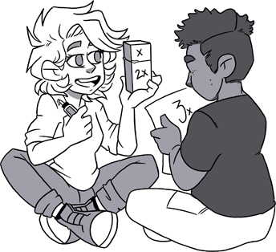

本章复习一些编程基础，考察条件在特定程序位置始终成立意味着什么，并学习如何编写简单规约。In this chapter, we review some basics of programming, consider what it means for a condition to always hold at a particular program point, and see how to write simple specifications.

## 1.0. 方法1.0. Methods

*方法*是规定某种行为的程序声明。例如，下面是名为Triple的方法声明：A *method* is a program declaration that prescribes some behavior. For instance, here is the declaration of a method named Triple:

**method** Triple(x: **int**) **returns** (r: **int**) {

**var** y := 2 * x;

r := x + y;

}

这个方法接收整数类型的*输入参数*x，返回同样为整数类型的*输出参数*r。方法的*方法体*位于方法签名之后的花括号内，由一列*语句*组成，给出方法的实现。这里的方法体包含两条语句。第一条语句声明局部变量y，并赋给它值2*x。第二条语句将输入参数x与局部变量y的和赋给输出参数r。This method takes an *in-parameter* x of type integer and returns an *out-parameter* r, also of type integer. The *body* of a method, given in curly braces after the method signature, is a list of *statements* that give the method's implementation. Here, the body consists of two statements. The first statement declares a local variable y to which it assigns the value 2*x. The second statement assigns the sum of the in-parameter x and the local variable y to out-parameter r.

## 习题1.0。Exercise 1.0.

如果x为10，方法会给r赋什么值？If x is 10, what value does the method assign to r?

在Dafny中，方法可以有任意多个输入参数和任意多个输出参数。在方法体中，输出参数充当局部变量，可以被赋值和读取。方法体结束时，输出参数的值就作为返回值交给调用者。输入参数当然也可以被读取，但不能在方法体中被重新赋值。In Dafny, methods can have any number of in-parameters and any number of out-parameters. In the body of the method, the out-parameters act as local variables and can be assigned and read. When the method body ends, whatever values the out-parameters have will be the values returned to the caller. The in-parameters can of course also be read, but they cannot be re-assigned in the method body.

下面这条语句展示了对该方法的调用：Here is a statement that shows a call to the method:

**var** t := Triple(18); // sets t to 54

我在语句旁边写了一条注释，说明这次调用的效果是把t设为54，即3乘以18。到下一章结束时，我们就能把这类注释转化成可以证明为真的条件。Next to the statement, I wrote a comment that the effect of this call is to set t to 54, which is 3 times 18. By the end of the next chapter, we will be able to turn comments like this into conditions that we can prove to be true.

## 1.1. 断言语句1.1. Assert Statements

查看上面的方法Triple，可以看出它返回值3*x。我们可以用**assert**语句在程序中显式写出这一观察（它有时称为*内联断言*，因为它将断言放在代码的特定位置）：By inspecting method Triple above, you can see that it returns the value 3*x. We can state this observation explicitly in the program using an **assert** statement (sometimes called an *inline assertion*, because it places an assertion at a particular point in the code):

**method** Triple(x: **int**) **returns** (r: **int**) {

**var** y := 2 * x;

r := x + y;

**assert** r == 3 * x;

}

使用断言（或者在某些其他语言中使用注释），把代码中重要而不显然的条件写下来，是良好的软件工程实践。写出条件有助于思考，也起到了文档的作用。It is good software-engineering practice to use assertions (or in some other languages, comments) to write down essential and non-obvious conditions in the code. Writing down the condition helps our thinking and serves as documentation.

在本书中，这类断言不仅仅是文档，它们还是*证明义务*。要将程序视为正确，我们必须*证明*：每次程序控制流到达断言时，所断言的条件都成立。证明应当适用于所在方法参数的所有可能值。这意味着，把*运行*程序作为证明方式，永远都远远不够：要尝试的输入实在太多。相反，我们会构造数学证明，用符号*变量*而非具体值来代表程序输入。Throughout this book, these kinds of assertions are more than just documentation. They are *proof obligations*. For the program to be considered correct, we must *prove* that the asserted condition holds every time the program's control flow reaches the assertion. The proof should apply for all possible values of the enclosing method's parameters. This means that *running* the program is always going to be hopelessly insuﬃcient as a form of proof—there are far too many inputs to try. Instead, we will construct a mathematical proof where we use symbolic *variables*, not specific values, to stand for the program's inputs.

当你在Dafny程序中写下断言时，验证器会立即尝试替你证明它。对于Triple中的断言，验证器很容易就能构造证明，从而确认所断言的条件始终成立。在其他情况下，如果验证器无法证明断言（例如，把上面的条件改成3*x + 1），就会给出错误消息。When you write an assertion in a Dafny program, the verifier immediately tries to do the proof for you. For the assertion in Triple, the verifier easily constructs the proof, which confirms that the asserted condition always holds. In other cases, if the verifier cannot prove the assertion (for example, if we change the condition above to 3*x + 1), then it produces an error message.

## 习题1.1。Exercise 1.1.

在Dafny IDE中编写方法Triple。如果没有输入错误，你应该会在底部看到“verified”（已验证）的提示。将所断言的条件改为3 * x + 1。会发生什么？Write the method Triple in the Dafny IDE. If you don't introduce any typos, you should see the indication “verified” at the bottom. Change the asserted condition to 3 * x + 1. What happens?

## 1.2. 与验证器协作1.2. Working with the Verifier

收到程序验证器的错误消息时，我们需要找出问题（换句话说，需要调试验证过程），并采取补救措施。这两件事都可能很困难。When receiving an error message from the program verifier, we need to figure out the problem (in other words, we need to debug the verification) and take some recourse. Both of these can be diﬃcult.

如果问题并非一目了然，可以试着在程序的不同位置写下更多断言来查明原因。例如，可以在上述两条赋值语句之间再加一条断言。写下断言，相当于询问验证器：“你知道这个条件在这个程序位置（始终）成立吗？”If the problem isn't immediately obvious, we can try to figure out the problem by writing more assertions at various points in the program. For example, we might add another assertion between the two assignment statements above. Writing down an assertion amounts to asking the verifier, “do you know that this condition (always) holds at this program point?”.

有时，分析使我们发现代码中的错误；有时，我们意识到自己写下的条件不正确，从而加深对代码的理解；还有时，条件事实上可能始终成立，但信息不足以得出这一结论。这时通常的补救方法是写出一些前置条件，或加强某个不变式，随后几章会看到许多这样的例子。最后，有时问题可能在于验证器还不够“聪明”，无法自动完成证明，这时我们需要给予帮助。对于随后几章讨论的那类程序，验证器往往表现很好；但对于更复杂的程序，常常需要提供引理或证明步骤。In some cases, our analysis results in detecting an error in the code. In other cases, we realize that the condition we wrote down isn't correct, which sharpens our understanding of the code. In yet other cases, the condition may in fact always hold but there isn't enough information to conclude this. The typical recourse in such cases is to write some preconditions or to strengthen some invariant; we will see many examples of this in the next few chapters. Finally, in some cases, the problem may be that the verifier isn't “clever” enough to do the proof automatically, in which case we'll need to help it along. The verifier tends to do very well on the sorts of programs discussed in the next several chapters, but for more intricate programs, it will frequently be necessary to supply lemmas or proof steps.

应当把验证器给出的任何错误消息，理解为代码、规约或证明所需的辅助声明中*可能*存在错误，而不是程序必然不会按预期工作的证据。总的来说，可以把程序验证器看作一位认真投入、注重细节、总在你身后查看代码的同事。有时它能迅速发现错误；另一些时候，就像最优秀的同事也会遇到的情况一样，验证器无法弄明白，因此需要我们提供进一步的信息作为提示，帮助解释我们为何认为程序是正确的。Any error message received from the verifier should be understood as a *possible* error (in the code, in a specification, or in some auxiliary declaration required for the proof), rather than as evidence that the program will not work as intended. In general, think of the program verifier as a dedicated, detailed-oriented colleague who is constantly peering over your shoulder. Sometimes, it detects errors quickly. Other times, just like the best of our colleagues, the verifier isn't able to figure it out, and thus we need to supply further information as hints that help explain why we think the program is correct.

到达失败断言（即其条件求值为**false**的断言）的程序轨迹是错误的，不会越过该断言继续执行。换句话说，只有条件成立的控制流，才会在断言之后继续。为说明这一点，考虑以下程序：A program trace that reaches a failing assertion (that is, an assertion whose condition evaluates to **false**) is erroneous and does not continue past the assertion. In other words, the only control flows that continue after an assertion are ones where the condition holds. For illustration, consider the program

**method** Triple(x: **int**) **returns** (r: **int**) {

**var** y := 2 * x;

r := x + y;

**assert** r == 10 * x; // error

**assert** r < 5;

**assert false**; // error

}

第一个断言并非始终成立，因此验证器发出错误消息。对于第一个断言确实成立的任何轨迹（即3*x == 10*x，它恰好在x == 0时成立），第二个断言也成立。因此验证器不会对第二个断言提出异议。但即使通过了前两个断言的轨迹，也无法通过第三个断言，所以验证器会对此提出异议。The first assertion does not always hold, so the verifier issues an error message. For any trace where the first assertion does in fact hold (namely, when 3*x == 10*x, which holds just when x == 0), the second assertion holds as well. Therefore, the verifier has no complaint about the second assertion. But even the traces that pass both of the first assertions do not pass the third, so the verifier will issue a complaint about it.

## 习题1.2。Exercise 1.2.

在Dafny IDE中亲自尝试这个包含三条**assert**语句的程序。修改第二个断言，使验证器对前两个断言提出异议，但不对第三个断言提出异议。Try this program with the three **assert** statements for yourself in the Dafny IDE. Change the second assertion to make the verifier complain about the first two assertions but not about the third.

## 1.3. 控制路径1.3. Control Paths

目前看到的简单代码示例，都只有一条包含一系列语句的控制路径。有了**if**语句和其他条件语句，一段代码就可能包含许多控制路径。当沿*所有*控制路径的轨迹都正确时，程序才正确。The simple code examples we've seen so far have a single control path containing a sequence of statements. With **if** statements and other conditional statements, a piece of code can contain many control paths. A program is correct when the traces along *all* control paths are correct.

例如，下面再次给出方法Triple，这次使用条件语句：<sup>0</sup>For example, here is method Triple again, this time using a conditional statement:<sup>0</sup>

**method** Triple(x: **int**) **returns** (r: **int**) {

**if** x == 0 {

r := 0;

} **else** {

**var** y := 2 * x;

r := x + y;

}

**assert** r == 3 * x;

}

**if**语句将程序轨迹分为经过“then”分支的轨迹（当x == 0时）和经过“else”分支的轨迹（当x != 0时）。程序正确性要求，无论采取哪个分支，所断言的条件都成立。The **if** statement divides the program traces into those that flow through the “then” branch (when x == 0) and those that flow through the “else” branch (when x != 0). Program correctness requires the asserted condition to hold regardless of which branch is taken.

对经过“then”分支的控制路径进行推理时，可以只关注x为0的情形，因为只有当x为0时，程序才会走这条路径。同样，对“else”分支推理时，可以只关注x不为0的情形，因为只有当x不为0时，程序才会走这条路径。When we reason about the control path through the “then” branch, we can confine our attention to the case where x is 0, because only when x is 0 can the program take that path. Likewise, when we reason about the “else” branch, we can confine our attention to the case where x is non-0, because only when x is non-0 can the program take that path.

普通**if**语句中的控制是*确定性的*，这意味着程序输入唯一确定所采取的控制路径。控制流也可以是*非确定性的*，也就是说，即使用相同输入反复运行程序，也可能产生不同轨迹。Control in the ordinary **if** statement is *deterministic*. This means that the program inputs uniquely determine the control path taken. Control flow can also be *nondeterministic*, which means that repeatedly running the program, even on the same input, may result in different traces.

Dafny的**if**-**case**语句是非确定性控制流的一个例子，其中允许各守卫条件重叠。下面这个过于曲折的Triple版本说明了这一点：An example of nondeterministic control flow is found in Dafny's **if**-**case** statement, where the guards are allowed to be overlapping. This is illustrated by the following, overly convoluted version of Triple:

**method** Triple(x: **int**) **returns** (r: **int**) {

**if** {

**case** x < 18 =>

**var** a, b := 2 * x, 4 * x;

r := (a + b) / 2;

**case** 0 <= x =>

**var** y := 2 * x;

r := x + y;

}

**assert** r == 3 * x;

}

对第一个分支推理时，可以假设x < 18，因为只有当x小于18时才会选择该分支。类似地，对第二个分支推理时，可以假设0 <= x，因为只有当x非负时才会选择该分支。如果x*既*小于18又非负，那么两个分支中的任何一个都有可能被选择；因此，要使断言正确，必须检查两条控制路径对于这样的x值都正确。在这个例子中，两个分支为r计算出相同的值，但一般而言，不同分支的行为可以大相径庭。When reasoning about the first branch, we can assume x < 18, because that branch is taken only if x is less than 18. Similarly, when reasoning about the second branch, we can assume 0 <= x, because that branch is taken only if x is non-negative. If x is *both* less than 18 and non-negative, then either branch can be chosen; therefore, in order for the assertion to be correct, both control paths must be checked to be correct for such values of x. In this example, both branches compute the same value for r, but in general, different branches can have vastly different behaviors.

关于最后这个例子，还有两点值得指出。第一，第一个分支使用了同时赋值：在给左侧变量赋值之前，先对所有右侧表达式求值。第二，**case**分支中声明的局部变量，其作用域仅限于该分支，即使该分支并没有用单独的一对花括号包围起来。Two other points are worth making about this last example. One point is that the first branch makes use of a simultaneous assignment, where the right-hand sides are all evaluated before the variables on the left are assigned. The other point is that the scope of local variables declared in a **case** branch is limited to that branch, even though the branch is not enclosed in separate curly-brace pairs.

## 1.4. 方法契约1.4. Method Contracts

方法（或函数、类型、模块）的*客户*，是想要使用该方法（或函数、类型、模块）的一段代码。考虑Triple方法的一个客户：A *client* of a method (or function or type or module) is a piece of code that wants to use the method (or function or type or module). Consider a client of the Triple method:

**method** Caller() {

**var** t := Triple(18);

**assert** t < 100;

}

查看前几节中Triple的方法体，可以看出t会被赋值为54，因此调用者的断言将成立。然而，按照良好的软件工程原则——*信息隐藏*，方法体被视为方法私有的内容，调用者不应查看它。这样，方法就能修改实现细节，而不影响调用者。By looking at the body of Triple in the previous sections, we can see that t will be assigned the value 54, and thus the caller's assertion will hold. However, by the good software-engineering principle of *information hiding*, the method body is considered to be private to the method and should not be looked at by callers. This allows the method to alter the details of its implementation without affecting callers.

## 习题1.3。Exercise 1.3.

使用第1.0节中Triple的定义和刚给出的Caller定义，验证器会作何反应？Using the definition of Triple from Section 1.0 and the definition of Caller just given, how does the verifier respond?

那么，如果不允许调用者窥视方法体，调用者怎样才能了解方法会做什么？答案是，方法还会声明一份*规约*。规约描述方法的行为，但抽去了方法体的细节。更确切地说，方法在调用者与实现之间采用一份“协议”，或称*契约*，说明调用者能够依赖什么。这样，方法作者就能灵活地描述方法接口，而不透露当前实现的细节。由于调用位置使用的是方法契约而不是方法体，我们称方法为*不透明的*。So, if a caller is not allowed to peek into the method body, how can the caller know anything about what the method will do? The answer is that the method additionally is declared with a *specification*. The specification describes the behavior of the method, but abstracts from the details of the method body. More precisely, a method uses an “agreement”, or *contract*, between the caller and implementation that says what the caller can rely on. The contract thus gives the method author flexibility to describe the interface to the method without divulging the details of the current implementation. Since the method contract, not the method body, is used at call sites, we say that the methods are *opaque*.

方法契约有两个基本部分：*前置条件*和*后置条件*。前置条件说明调用者何时可以合法地调用方法。它在每个调用位置都是一项证明义务；作为交换，在方法体开始时可以假定它成立。后置条件在方法体的每个返回位置都是一项证明义务；作为交换，在调用位置从该次调用返回时，可以假定它成立。A method contract has two fundamental parts: a *precondition* and a *postcondition*. The precondition says when it is legal for a caller to invoke the method. It is a proof obligation at every call site, and in exchange it can be assumed to hold at the start of the method body. The postcondition is a proof obligation at every return point from the method body, and in exchange it can be assumed to hold upon return from the invocation at the call site.

在我们的例子中，可以为Triple编写后置条件，使Caller能够证明其方法体中的断言。后置条件用**ensures**关键字引入：In our example, we can write a postcondition for Triple that lets Caller prove the assertion in its body. The postcondition is introduced with the **ensures** keyword:

**method** Triple(x: **int**) **returns** (r: **int**)

**ensures** r == 3 * x

{

**var** y := 2 * x;

r := x + y;

}

现在方法Caller通过验证，Triple也一样。Method Caller now verifies, and so does Triple.

我们的例子并不需要前置条件，但为了说明起见，仍然声明一个。前置条件用**requires**关键字引入：Our example does not warrant a precondition, but let us nevertheless declare one for illustration purposes. A precondition is introduced with the **requires** keyword:

**method** Triple(x: **int**) **returns** (r: **int**)

**requires** x % 2 == 0

**ensures** r == 3 * x

{

**var** y := x / 2;

r := 6 * y;

}

这个版本的Triple要求给定的x为偶数。事实上，新的实现体依赖于x的偶性：如果没有该前置条件，当x为奇数时，赋给r的值就会小于3*x（因为整数除法会进行舍入），验证器也会发出错误消息，指出Triple可能无法确立其后置条件。This version of Triple requires the given x to be even. Indeed, the new implementation body relies on the evenness of x—without the precondition, the value assigned to r would be less than 3*x for odd values of x (since integer division performs some rounding) and the verifier would issue an error message that Triple may fail to establish its postcondition.

## 习题1.4。Exercise 1.4.

删除（或注释掉）Triple的前置条件。验证器会给出什么错误？Remove (or comment out) the precondition of Triple. What error does the verifier give you?

## 习题1.5。Exercise 1.5.

写出两个比前置条件x % 2 == 0更强的替代条件，使方法Triple同样能通过验证。Write two stronger alternatives to the precondition x % 2 == 0 that also make the method Triple verify.

再来看几个例子。Let's take a look at some more examples.

### 1.4.0. 欠规约1.4.0. Underspecification

考虑以下方法规约：Consider the following method specification:

**method** Index(n: **int**) **returns** (i: **int**)

**requires** 1 <= n

**ensures** 0 <= i < n

前置条件说明，Index只能以正整数为参数调用。后置条件说明，Index(n)返回的i是一个大于等于0且小于n的数。The precondition says that Index can be called only on positive integers. The postcondition says that Index(n) will return i as some number between 0 and less than n.

## 边栏1.0Sidebar 1.0

本书会仔细区分：“0*到*n”表示i在半开区间0 <= i < n中的可能值，而“0*直至*n”表示两端均包含的区间0 <= i <= n。In this book, I'll be careful to say “0 *to* n” to mean the possible values of i in the half-open interval 0 <= i < n, and I will say “0 *through* n” to mean the inclusive interval 0 <= i <= n.

那么，究竟会返回从0到n之间的*哪个*数呢？规约没有说明。因此，对Index的调用进行推理时，我们要考虑所有这些值。从调用者的角度看，这个方法就仿佛是非确定性的。So, *which* number from 0 to n will be returned? The specification does not say. Therefore, when we reason about calls to Index, we consider all of these values. Viewed by the caller, it is as if this method were nondeterministic.

下面是该方法的一种实现方式：Here is one way to implement the method:

**method** Index(n: **int**) **returns** (i: **int**)

**requires** 1 <= n

**ensures** 0 <= i < n

{

i := n / 2;

}

这个实现是正确的：对于满足前置条件的每个可能输入值n，方法体都确立后置条件。This implementation is correct: for every possible input value n that satisfies the precondition, the method body establishes the postcondition.

下面是实现Index的另一种方式：Here is another way to implement Index:

**method** Index(n: **int**) **returns** (i: **int**)

**requires** 1 <= n

**ensures** 0 <= i < n

{

i := 0;

}

这个实现也正确。由于方法是不透明的——即调用者只能看到方法规约，看不到方法体——所以把Index的方法体从i := n / 2;改成i := 0;，不会影响任何调用者的正确性。This implementation is also correct. Because methods are opaque—that is, callers only get to see the specification of a method, not its body—it is fine to change the body of Index from i := n / 2; to i := 0; without affecting the correctness of any callers.

刚才考虑的两个实现都是确定性的。也就是说，对于给定输入，方法体以相同的方式计算输出。但由于方法是不透明的，调用者不能依赖这一点。例如，在Each of the two implementations we just considered is deterministic. That is, for a given input, the method body computes the output in the same way. But since methods are opaque, this is not something a caller can rely on. For example, in

**var** x := Index(50);

**var** y := Index(50);

**assert** x == y; // error

中，该断言无法证明，因为从Index的规约中，我们只知道the assertion cannot be proved, because all we know from the specification of Index is

0 <= x < 50 && 0 <= y < 50

却不知道x与y之间有任何联系。but we know of no connection between x and y.

虽然规约允许任何值，但实现可以是确定性的，而且通常确实如此。这个重要思想称为*欠规约*。它精确规定了调用者与实现之间的契约所允许的自由度。While the specification allows any value, the implementation can be—and most often is—deterministic. This important idea is called *underspecification*. It precisely specifies the freedom entailed by the caller-implementation contract.

### 1.4.1. 多个后置条件1.4.1. Multiple postconditions

考虑一个计算两个给定值中较小值的方法：Consider a method that computes the smaller of two given values:

**method** Min(x: **int**, y: **int**) **returns** (m: **int**)

**ensures** m <= x && m <= y

这份规约说明，返回值既不大于x，也不大于y。但它允许返回值比两者都小很多。This specification says that the value returned is no greater than either x or y. But it allows the value returned to be significantly smaller than both.

## 习题1.6。Exercise 1.6.

为Min编写一个实现，使其满足上面的后置条件，但返回值并不总是x和y的最小值。Write an implementation for Min that satisfies the postcondition above but is not always the minimum of x and y.

要使这份规约成为预期的最小值规约，还需要说明返回值是两个输入之一：To make the specification be the expected one for minimum, we also need to say that the value returned is one of the two inputs:

**method** Min(x: **int**, y: **int**) **returns** (m: **int**)

**ensures** m <= x && m <= y

**ensures** m == x || m == y

## 习题1.7。Exercise 1.7.

下面是一个方法的类型签名，它计算s为x与y之和，计算m为x与y的最大值：Here is the type signature of a method to compute s to be the sum of x and y and m to be the maximum of x and y:

**method** MaxSum(x: **int**, y: **int**) **returns** (s: **int**, m: **int**)

(a) 写出这个方法预期的后置条件。(b) 编写一个方法，以1928和1为输入实参调用MaxSum。在调用之后添加一个断言，说明你预期两个输出参数应当为何值。如果验证器指出该断言可能被违反，就回到(a)改进规约。这是一种很有用的“规约测试”方法。注意，你是用验证器测试规约，而不是通过运行程序来测试。(c) 为MaxSum编写实现。(a) Specify the intended postcondition of this method. (b) Write a method that calls MaxSum with the input arguments 1928 and 1. Follow the call with an assertion about what you expect the two out-parameters to be. If the verifier complains that the assertion may be violated, go back to (a) to improve the specification. This is a useful way to “test the specification”. Note, you're testing the specification by using the verifier, not by running the program. (c) Write an implementation for MaxSum.

## 习题1.8。Exercise 1.8.

考虑一个方法，试图根据习题1.7中MaxSum的返回值，重建实参x和y。换句话说，考虑具有以下类型签名和后置条件的方法：Consider a method that attempts to reconstruct the arguments x and y from the return values of MaxSum in Exercise 1.7. In other words, consider a method with the following type signature and postcondition:

**method** ReconstructFromMaxSum(s: **int**, m: **int**) **returns** (x: **int**, y: **int**)

**ensures** s == x + y

**ensures** (m == x || m == y) && x <= m && y <= m

(a) 尝试编写这个方法的方法体。你会发现无法做到。为方法编写适当的前置条件，使你能够实现它。(b) 编写以下测试框架，测试方法的规约：(a) Try to write the body for this method. You will find you cannot. Write an appropriate precondition for the method that allows you to implement the method. (b) Write the following test harness to test the method's specification:

**method** TestMaxSum(x: **int**, y: **int**) {

**var** s, m := MaxSum(x, y);

**var** xx, yy := ReconstructFromMaxSum(s, m);

**assert** (xx == x && yy == y) || (xx == y && yy == x);

}

怎样修改ReconstructFromMaxSum的规约，才能使测试框架中的断言成立？How can you change the specification of ReconstructFromMaxSum to allow the assertion in the test harness to succeed?

## 1.5. 函数1.5. Functions

还有一种核心声明构造会经常出现：函数。正如你从数学中了解的那样，*函数*表示由给定实参计算出的值。函数的关键性质是*确定性*，也就是说，以相同实参进行的任意两次函数调用，都会得到相同值。There's one more central declaration construct we'll see often: functions. As you know from mathematics, a *function* denotes a value computed from given arguments. The key property of a function is that it is *deterministic*, that is, any two invocations of the function with the same arguments result in the same value.

下面是Dafny中函数声明的一个例子：Here is an example function declaration in Dafny:

**function** Average(a: **int**, b: **int**): **int** {

(a + b) / 2

}

注意，方法声明若干输出参数，而函数声明的是结果类型；方法体是语句，而函数体则是表达式。Note that, whereas a method is declared to have some number of out-parameters, a function instead declares a result type, and whereas a method body is a statement, the body of a function is an expression.

函数可以用在表达式中，因此可以写出如下规约：Functions can be used in expressions, so we can write a specification like this:

**method** Triple’(x: **int**) **returns** (r: **int**)

**ensures** Average(r, 3 * x) == 3 * x

## 边栏1.1Sidebar 1.1

Dafny中的标识符可以含有’字符。这里我声明了一个名为Triple’的方法，可以读作“三倍撇”。Identifiers in Dafny can contain the ’ character. Here, I declared a method named Triple’, which you can pronounce as “triple prime”.

## 习题1.9。Exercise 1.9.

Triple’的规约与Triple的规约并不相同。(a) 为Triple’编写一个正确的方法体，但不满足Triple的规约。(b) 如何以最少修改加强Triple’的规约，使它与Triple的规约等价？(c) 如何用Dafny证明(b)中的规约确实等价？The specification of Triple’ is not the same as that of Triple. (a) Write a correct body for Triple’ that does not meet the specification of Triple. (b) How can you strengthen the specification of Triple’ with minimal changes to make it equivalent to the specification of Triple? (c) How can you use Dafny to prove that the specifications in (b) are indeed equivalent?

上面的例子突出了Dafny中方法与函数的另一个重要区别：方法不透明，而函数*透明*。这是必要的，因为如果调用者只能根据函数规约来理解函数，那么函数的规约就永远无法使用函数，这将严重限制可以对函数作出的描述。The example above highlights another important difference between methods and functions in Dafny: whereas methods are opaque, functions are *transparent*. This is necessary, because if callers had to understand a function only from its specification, then the specification of functions could never make use of functions, which would severely limit what can be said about a function.

尽管如此，函数仍然可以有规约。特别重要的是函数的前置条件，它说明何种情况下允许调用函数。例如，可以把Average的使用限制为非负实参：Nevertheless, a function can have specifications. Of special importance is the function's precondition, which says under which circumstances the function is allowed to be invoked. For example, we can restrict uses of Average to non-negative arguments:

**function** Average(a: **int**, b: **int**): **int**

**requires** 0 <= a && 0 <= b

{

(a + b) / 2

}

**method** Triple(x: **int**) **returns** (r: **int**)

**ensures** r == 3 * x

{

**if** 0 <= x {

r := Average(2 * x, 4 * x);

} **else** {

r := -Average(-2 * x, -4 * x);

}

}

函数前置条件在调用位置受到强制检查，与方法前置条件一样。Function preconditions are enforced at call sites, just as for method preconditions.

由于断言、前置条件和后置条件都使用布尔条件，我们经常会声明布尔函数（即结果类型为**bool**的函数），用于规约。布尔函数也称为*谓词*，Dafny为此保留了一个关键字：Since assertions, preconditions, and postconditions use boolean conditions, it frequently happens that we declare boolean functions (that is, a function with result type **bool**) for use in specifications. A boolean function is also known as a *predicate* and Dafny reserves a keyword for this purpose: the meaning of

**predicate** IsEven(x: **int**) {

x % 2 == 0

}

的含义完全相同于is identical to

**function** IsEven(x: **int**): **bool** {

x % 2 == 0

}

## 1.6. 编译构造与幽灵构造1.6. Compiled versus Ghost

基础介绍的最后，再讲一个重要概念。对程序进行推理时，经常需要使用比编译器或运行时所需更多的信息。Dafny语言为此集成了许多特性。仅用于规约的声明、变量、语句等，称为*幽灵*构造。验证器会考虑所有幽灵构造，而编译器在生成可执行代码时，会擦除全部幽灵构造。进入可执行代码的程序构造，则称为*编译*构造或*非幽灵*构造。I'll end our introduction of basics with one more important concept. When reasoning about a program, it is frequently necessary to make use of more information than is needed by the compiler or at run time. The Dafny language integrates many features for this purpose. A declaration, variable, statement, etc., that is used only for specification purposes is called a *ghost*. The verifier takes all ghosts into account, whereas the compiler erases all ghosts when it emits executable code. Program constructs that make it into the executable code are referred to as *compiled* or *non-ghost*.

我们已经见过几种幽灵构造。前置条件和后置条件（由**requires**和**ensures**子句声明）都是幽灵构造。它们用于规定程序行为，并在调用者和实现之间建立契约。我们也见过一种幽灵语句：**assert**。We have seen several ghost constructs already. Pre- and postconditions (declared by **requires** and **ensures** clauses) are ghost. They are used to specify the behavior of the program and establish a contract between callers and implementations. We have also seen a ghost statement: **assert**.

前置条件、后置条件和断言在编写程序时由验证器检查。由于它们是幽灵构造，编译器会擦除它们，因此不会产生运行时开销。即使不担心运行时开销，也没有必要在运行时检查断言，因为一旦通过验证器，就已知这些断言在程序的每条轨迹中都成立。Pre- and postconditions and assertions are checked by the verifier when you write the program. Since they are ghost, they are erased by the compiler and thus they bear no run-time cost. Even if we were not worried about run-time cost, there would be no point in checking assertions at run-time, because once they pass the verifier, the assertions are known to hold in every trace of the program.

Dafny中的多种声明，都同时具有幽灵形式和编译形式。它们看起来大致相同，验证器对它们的处理也相同，但使用目的往往不同。要把变量、（输入或输出）参数、方法、函数或谓词声明为幽灵，只需在其声明前添加关键字**ghost**。为了能够擦除幽灵构造，Dafny会检查编译代码不依赖幽灵构造。例如，如下所示：Several kinds of declarations in Dafny exist in both a ghost form and a compiled form. They look mostly the same and are treated the same by the verifier, but the purpose for using them is often different. To declare a variable, (in- or out-)parameter, method, function, or predicate as a ghost, simply precede its declaration with the keyword **ghost**. To make the erasure of ghosts possible, Dafny checks that compiled code does not rely on ghost constructs. For example, as illustrated here:

**method** IllegalAssignment() **returns** (y: **int**) {

**ghost var** x := 10;

y := 2 * x; // error: cannot assign to compiled

// variable using a ghost

}

程序不允许在给编译变量赋值的右侧表达式中使用幽灵变量。a program is not allowed to use a ghost variable in the right-hand side of an assignment to a compiled variable.

## 习题1.10。Exercise 1.10.

下面代码片段中的函数和方法都声明为编译形式。The function and method in the following code snippet are both declared as compiled.

**function** Average(a: **int**, b: **int**): **int** {

(a + b) / 2

}

**method** Triple(x: **int**) **returns** (r: **int**)

**ensures** r == 3 * x

{

r := Average(2 * x, 4 * x);

}

(a) 修改这个例子，将Average声明为幽灵。会得到什么错误消息？(b) 将Average和Triple都声明为幽灵。这是否合法？(c) 将Average声明为编译形式，将Triple声明为幽灵。这是否合法？(a) Change this example to declare Average as ghost. What error message do you get? (b) Declare both Average and Triple as ghost. Is that legal? (c) Declare Average as compiled and Triple as ghost. Is that legal?

### 1.6.0. 幽灵方法示例1.6.0. Ghost-method example

再考虑贯穿本章的例子的另一个版本，以说明幽灵构造的一种（有点傻的）用法：Let me illustrate a (silly) use of ghost constructs by considering another version of our running example:

**method** Triple(x: **int**) **returns** (r: **int**)

**ensures** r == 3 * x

{

**var** y := 2 * x;

r := x + y;

**ghost var** a, b := DoubleQuadruple(x);

**assert** a <= r <= b || b <= r <= a;

}

**ghost method** DoubleQuadruple(x: **int**) **returns** (a: **int**, b: **int**)

**ensures** a == 2 * x && b == 4 * x

{

a := 2 * x;

b := 2 * a;

}

这个幽灵方法将2*x和4*x分别计算到两个输出参数中。可以看到，除了方法声明前的**ghost**关键字外，Double-Quadruple看起来就像普通的编译方法。This ghost method computes 2*x and 4*x into the method's two out-parameters. As you can see, other than the **ghost** keyword in front of the method declaration, Double-Quadruple looks like an ordinary, compiled method.

这个版本的Triple调用幽灵方法，将其输出参数存入两个局部幽灵变量a和b。随后的断言同时提及幽灵变量和编译变量，以表达预期成立的条件。编译这段代码时，Triple的后置条件、Triple的局部变量a和b、对DoubleQuadruple的调用、该断言以及整个DoubleQuadruple方法，都会被擦除。This version of Triple calls the ghost method, storing its out-parameter in two local ghost variables, a and b. The subsequent assertion mentions both ghost and compiled variables to express a condition that is expected to hold. When this code is compiled, the postcondition of Triple, Triple's local variables a and b, the call to DoubleQuadruple, the assertion, and the entire DoubleQuadruple method are erased.

## 边栏1.2Sidebar 1.2

上面的例子（以及第1.4.0节中的Index例子）展示了我们将经常使用的一种记法特性：比较运算符的*链式连接*。例如，可以把<、<=和==运算符连在一起，而不必重复共有的操作数。其含义是将相邻各项之间的比较作合取。例如，表达式The example above (and also the Index example of Section 1.4.0) illustrates a notational feature that we will make frequent use of: the *chaining* of comparison operators. For example, the operators <, <=, and == can be chained together without repeating the shared operands. The meaning is that of conjoining the pairwise comparisons. For example, the expression

0 <= i < j < a.Length == N

与下面的表达式含义相同：has the same meaning as

0 <= i && i < j && j < a.Length && a.Length == N

但更容易阅读。上面最后一个版本的Triple中的**assert**语句，也可以写成but is easier to read. The **assert** statement in our last version of Triple above could also have been written

**assert** (a <= r && r <= b) || (b <= r && r <= a);

## 1.7. 小结1.7. Summary

本章介绍了方法、函数、前置条件与后置条件、简单语句与控制流，以及幽灵构造和编译构造的区别。In this chapter, I have introduced methods, functions, pre- and postconditions, simple statements and control flow, and the distinction between ghost and compiled.

方法具有任意多个输入和输出参数。它用前置条件和后置条件编写规约，方法体是一列语句。方法体不透明，也就是说，调用者仅依据规约对方法调用进行推理。方法的行为可以是非确定性的。A method has any number of in- and out-parameters. It is specified with pre- and postconditions, and its body is a list of statements. The body is opaque, which says that callers reason about method invocations in terms of the specification alone. The behavior of a method can be nondeterministic.

函数具有任意多个输入参数，且恰有一个结果值。它可以有规约，函数体是表达式。函数体透明，也就是说，对函数调用进行推理时，调用者可以查看函数体。函数的行为是确定性的。结果类型为布尔类型的函数称为谓词。A function has any number of in-parameters and exactly one result value. It can have a specification, and its body is an expression. The body is transparent, which says that callers can look into the function body when reasoning about function invocations. The behavior of a function is deterministic. A function with a boolean result type is called a predicate.

**assert**语句指出程序员预期成立的一个条件。它产生一项证明义务，必须先完成证明，才能编译并运行程序。因此，在已验证的程序中，你可以依赖每个所断言的条件都成立。An **assert** statement points out a condition that a programmer expects to hold. It gives rise to a proof obligation that must be proved before you can compile and run your program. Thus, in a verified program, you can rely on every asserted condition to hold.

前置条件和后置条件描述方法的行为。前置条件通过声明一个必须在每个调用位置证明的条件，限制方法的使用方式。后置条件通过声明一个必须对贯穿方法体的每条控制路径证明的条件，限制方法实现的行为。Pre- and postconditions describe the behavior of methods. The precondition limits the uses of a method by declaring a condition that must be proved at every call site. The postcondition limits the behaviors of the method implementation by declaring a condition that must be proved for every control path through the method body.

幽灵构造用于解释程序的预期行为。验证器会使用它，编译器则会擦除它。幽灵构造包括前置条件、后置条件和**assert**语句。A ghost is a construct that serves to explain the intended behavior of a program. It is used by the verifier, but erased by the compiler. Ghost constructs include pre- and postconditions and **assert** statements.

## 习题1.11。Exercise 1.11.

(a) 对于这个程序中的两个断言，验证器会怎么说？(a) What does the verifier have to say about the two assertions in this program?

**function** F(): **int** {

29

}

**method** M() **returns** (r: **int**) {

r := 29;

}

**method** Caller() {

**var** a := F();

**var** b := M();

**assert** a == 29;

**assert** b == 29;

}

(b) 解释原因。(c) 如何修改程序，使两个断言都通过验证？(b) Explain why. (c) How can you change the program to make both assertions verify?

## 注记Notes

各编程语言对过程式例程的称呼并不一致。例如，C和Python把一段代码称为“函数”，而Rust和Go则把接收一个接收者参数（如**this**）的“函数”称为“方法”。本书中，“方法”以代码作为其方法体，而“函数”以表达式作为其函数体。重要的是，本书中的“函数”（也确实就是Dafny中的**function**）具有数学函数的行为。方法或函数是否带有接收者参数，取决于它是否被声明为某个类型的成员（到第16章才会看到接收者参数）。Programming languages do not agree on what to call procedural routines. For example, C and Python refer to a body of code as a “function”, and Rust and Go use the word “method” for a “function” that takes a receiver parameter (like **this**). In this book, a “method” has code for its body, and a “function” has an expression for its body. Importantly, a “function” in this book (and, indeed, a **function** in Dafny) behaves like a mathematical function. Whether or not a method or function has a receiver parameter depends on whether or not it's declared as a member of a type (we'll have to wait until Chapter 16 before we see a receiver parameter).

有副作用的方法不适合用于规约。由于Java只有方法，Java建模语言（JML）[31]允许把方法标记为“纯”，使其能够用于规约，近似于数学函数。OpenJML工具还支持给方法添加“function”标记，将它声明为类似函数的形式[32]。A method with side effects is inappropriate for use in specifications. Since Java only has methods, the Java Modeling Language (JML) [31] allows a method to be marked as “pure”, which makes it usable in specifications, approximately like a mathematical function. The OpenJML tool also supports a “function” mark-up for a method, which declares it to be like a function [32].

在WhyML[20]和F*[53]中，语句与表达式并无区别。这些语言转而依赖其他机制（分别是区域和效应类型），跟踪其程序函数中可能发生的状态修改。In WhyML [20] and F* [53], there is no distinction between statements and expressions. Instead, these languages rely on other mechanisms (regions and effect types, respectively) to keep track of the state mutations that are possible in their program functions.

把前置条件、后置条件和证明断言写成程序文本一部分的思想由来已久。例如，它们在早期程序证明中以注释形式出现（例如[51, 88]）。影响深远的CLU语言[87]的标准文档风格包含前置条件和后置条件（以及第2部分将介绍的**modifies**子句的一种形式）。面向可验证程序的Euclid语言，将前置条件和后置条件作为语法的一部分予以支持[74]。VDM[67]和Larch[57]强调规约在程序设计中的作用。更多历史注记，可参阅一篇关于行为规约语言的综述论文[59]。The idea of writing pre- and postconditions and proof assertions as part of a program text is old. For example, they are featured as comments in early program proofs (e.g., [51, 88]). The standard documentation style of the influential language CLU [87] includes pre- and postconditions (and a form of the **modifies** clauses we'll see in Part 2). The Euclid language for verifiable programs supports pre- and postconditions as part of its syntax [74]. The role of specifications in the design of programs in emphasized by VDM [67] and Larch [57]. For additional historical notes, I refer you to a survey paper on behavioral specification languages [59].

是Bertrand Meyer的Eiffel语言及其配套的*契约式设计*方法，推广了在程序文本中编写前置条件和后置条件的思想[89]。调用者与实现之间的这些契约，使用普通语言的表达式语法来编写，这一思想影响了JML[66]和Spec#[13]的设计。It was Bertrand Meyer's Eiffel language and the accompanying *Design by Contract* methodology that popularized the idea of writing pre- and postconditions in the program text [89]. These contracts between callers and implementations are written using the ordinary language syntax for expressions, an idea that influenced the designs of JML [66] and Spec# [13].

幽灵变量和幽灵代码的使用，几十年来一直是规约领域口耳相传的知识。它们有时采用不同名称。例如，Owicki和Gries将其称为“辅助”变量[106]。在SPARK[43]和WhyML[20]中，幽灵函数称为“逻辑函数”。关于幽灵声明的更广泛讨论，参见[48, 59]。The use of ghost variables and ghost code has been part of specification folklore for decades. They sometimes go by different names. For example, Owicki and Gries called them “auxiliary” variables [106]. In SPARK [43] and WhyML [20], ghost functions are known as “logical functions”. For a wider perspective on ghost declarations, see [48, 59].

最后，关于整数，有一点重要说明。本书始终使用的Dafny类型**int**是*无界的*。这意味着数的行为与数学中相同，没有最大值或最小值。所以，如果Dafny程序计算一个很大的数（也许使用第3.3.1节的Ackermann函数）、将若干数相加（如第12.3节），或者只做把给定参数乘以三这样看似无害的事情（如本章的Triple方法），你都不必担心结果的数值过大。（不过，如果数*大到*计算机没有足够内存来表示它们😮，程序就会停止。Dafny不会检查你是否有足够资源来运行程序。）Dafny还支持*有界整数*，例如用32位能表示的整数，但本书不会使用它们。有些编程语言只支持无界整数（如Python），有些只支持有界整数（如C和Java），还有些验证语言同时支持两者（如SPARK和JML）。Lastly, an important remark about integers. Dafny's type **int**, which I use throughout the book, is *unbounded*. This means that the numbers behave as in mathematics, without any maximum or minimum value. So, if your Dafny program computes a large number (perhaps using the Ackermann function in Section 3.3.1), adds up numbers (like in Section 12.3), or does something as innocent as tripling the value of a given parameter (like method Triple in this chapter), you don't have to worry that the magnitude of the result will be too large. (Well, if numbers become *so* large that your computer doesn't have enough memory to represent them 😮, your program will halt. Dafny does not check that you have enough resources to run your programs.) Dafny additionally supports *bounded integers*, like those you can represent using 32 bits, but I won't use them in this book. Some programming languages support only unbounded integers (e.g., Python), some support only bounded integers (e.g., C and Java), and some verification languages support a mix of the two (e.g., SPARK and JML).

<sup>0</sup>注意，与一些其他流行语言不同，Dafny不要求用括号包围**if**的守卫条件。不加括号，程序文本看起来更简洁。<sup>0</sup>Note that, unlike some other popular languages, Dafny does not require the guard condition of **if** to be surrounded in parentheses. The program text looks cleaner without them.

# 第2章 形式化Chapter 2 Making It Formal

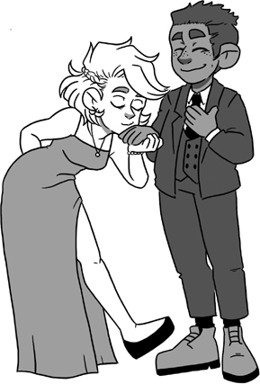

本章为前一章非形式化描述的内容提供形式化基础。我们用数学公式精确给出程序的含义，称这些公式给出了程序语句的*语义*。This chapter gives the formal underpinnings of what the previous chapter described informally. The meaning of programs is given precisely with mathematical formulas. These are said to give the *semantics* of the program statements.

本书的推理始终基于所谓的*Floyd逻辑*。它用布尔公式描述每条语句之前和之后的已知信息，使我们能够把对程序的推理分解为对程序中各条语句的推理。在此过程中，我将定义*Hoare三元组*和*最弱前置条件*，前者为理解语义提供良好指引，后者为自动化程序推理提供方便的方法。Throughout this book, the reasoning is based on what is called *Floyd logic*. It uses boolean formulas to describe what is known before and after each statement, which allows us to break down the reasoning about programs into reasoning about individual statements of the program. Along the way, I will define *Hoare triples*, which give a good guide to understanding semantics, and *weakest preconditions*, which give convenient ways to automate program reasoning.

程序语义的研究，似乎过于关注琐碎细节。不妨把它看作竖式乘法：它详细规定计算某个结果的步骤。对许多问题应用竖式乘法之后，你会对乘法有更深入的理解，进而意识到有些步骤可以走捷径。更重要的是，你随后就能把乘法用于日常问题。使你能解决问题的，并非竖式乘法的细小步骤，而是你对乘法的熟悉程度。因为你能完成这些步骤，你就知道有一种办法可以详细检查某个结果；但在实践中，你会用计算器或电子表格替你做乘法。The study of program semantics may seem overly concerned with picky details. Think of it as long multiplication—it prescribes steps for computing something in detail. Once you've applied long multiplication on many problems, you develop a deeper understanding of multiplication. You then realize that some steps can be replaced by shortcuts. More importantly, you can then put multiplication to use in daily problems. It is not the tiny steps of long multiplication that let you solve problems, but it is your familiarity with multiplication that does. Because you can carry out the steps, you know of a way to check something in detail, but in practice you use a calculator or spreadsheet to perform multiplication for you.

程序证明也是如此。完成那些细小步骤，会让你看清程序推理是如何进行的。如果对某处不确定，可以回到基础步骤，使自己确信程序正确（或发现错误）。不过在实践中，你通常会使用自动程序验证器，替你进行语义计算。Program proving is like that. Carrying out the small steps lets you see how program reasoning is done. If you're unsure of something, you can return to the foundational steps and convince yourself of your program's correctness (or find mistakes). In practice, however, you will typically use an automated program verifier that performs the semantic computations for you.

让我们进入细节。程序语义，我们来了！Let's get on with the details. Program semantics, here we come!

## 2.0. 程序状态2.0. Program State

程序有几种*变量*，包括方法的输入和输出参数，以及方法体中声明的局部变量。在程序某个位置可以使用的变量，称为在该程序位置*处于作用域内*。某个程序位置的*状态*，就是对该位置作用域内各变量的一次赋值。A program has several kinds of *variables*. These include the in- and out-parameters of methods and the local variables declared in a method body. The variables that can be used at a point in a program are said to be *in scope* at that program point. The *state* at a program point is a valuation of the variables in scope at that program point.

为说明这一点，考虑以下方法：For illustration, consider the following method:

**method** MyMethod(x: **int**) **returns** (y: **int**)

**requires** 10 <= x

**ensures** 25 <= y

⓪

{ ①

**var** a, b;

②

a := x + 3;

③

**if** x < 20 {

④

b := 32 - x;

⑤

} **else** {

⑥

b := 16;

⑦

}

⑧

y := a + b;

⑨

} ⑩

进入这个方法时，即标为⓪的程序位置，只有方法的输入参数（x）在作用域内。刚进入方法体内部的程序位置①，输入和输出参数（x和y）都在作用域内。在声明局部变量a和b的语句之后，程序位置②的作用域包含x、y、a和b。程序位置③至⑨也一样。退出方法时，在程序位置⑩，局部变量已离开作用域，因此作用域再次只包含参数（x和y）。On entry to this method, that is, at the program point labeled ⓪, only the method's in-parameter (x) is in scope. Just inside the method body, at program point ①, both in- and out-parameters (x and y) are in scope. At program point ②, after the statement that declares local variables a and b, the scope consists of x, y, a, and b. The same is true at program points ③ through ⑨. On exit from the method, at program point ⑩, the local variables have gone out of scope so the scope once again consists of just the parameters (x and y).

程序位置⓪的状态称为方法的*初始状态*，它是对x的一次赋值。例如，x可以为18或37。如果它为37，那么程序位置⑨的状态就是：x为37、y为56、a为40、b为16。此外，⑩处的状态称为方法的*最终状态*，此时x为37、y为56。沿方法体跟踪程序执行，就可以确定这些状态。The state at program point ⓪, which is called the *initial state* of the method, is a valuation of x. For example, x may be 18 or 37. If it is 37, the state at program point ⑨ is 37 for x, 56 for y, 40 for a, and 16 for b. Moreover, the state at ⑩, which is called the *final state* of the method, is then 37 for x and 56 for y. You can determine these states if you trace the program execution through the method body.

## 习题2.0。Exercise 2.0.

如果初始程序状态为x取18，那么⑨处的程序状态和最终程序状态分别是什么？If the initial program state is 18 for x, what is the program state at ⑨ and what is the final program state?

如前一章所述，方法调用者负责确立方法的前置条件。因此，我们知道初始状态满足前置条件。例如，初始状态不可能是x取2，因为如果x为2，10 <= x就不成立。As we saw in the previous chapter, callers of a method are responsible for establishing the method's precondition. Consequently, we know the initial state satisfies the precondition. For example, the initial state cannot be 2 for x, because 10 <= x does not hold if x were 2.

前一章还讲过，方法实现负责确立方法的后置条件。因此，要认定MyMethod已正确实现，必须检查：对于每个可能的初始状态，沿方法体的每条可能轨迹，25 <= y都在状态⑩中成立。As we also saw in the previous chapter, a method implementation is responsible for establishing the method's postcondition. Consequently, to declare MyMethod to be correctly implemented, we must check that 25 <= y holds in state ⑩ for every possible trace through the method body, for every possible initial state.

如果不得不逐一尝试各条轨迹（例如从x为18或37开始的轨迹），就无法合理地确定这一点。我们需要一种同时推理许多状态的方法。这可以用布尔表达式来实现。更确切地说，我们用布尔表达式表示使该表达式求值为**true**的那些状态。例如，布尔表达式15 <= x <= 40表示x的值处于15直至40范围内的所有初始状态。We cannot reasonably determine this if we had to try out traces (like those starting from x being 18 or 37) one at a time. Instead, we need a way to reason about many states at a time. This is done using boolean expressions. More precisely, we use a boolean expression to denote those states that make the boolean expression evaluate to **true**. For example, the boolean expression 15 <= x <= 40 represents all initial states where the value of x lies in the range 15 through 40.

布尔表达式也称为*逻辑公式*（或简称*公式*），或称*谓词*，其含义就是对给定状态求值为**false**或**true**的表达式。也可以把谓词看作对*一组状态的刻画*。Another name for a boolean expression is *logical formula* (or just *formula*) or *predicate*, which simply means an expression that for a given state evaluates to either **false** or **true**. You can also think of a predicate as *characterizing a set of states*.

我们不再跟踪一个状态如何通过程序，而是跟踪一个*谓词*如何通过程序。本章主要目的就是教你如何做到这一点。下面是我们希望能够弄清楚的一些问题：Instead of tracing a state through the program, we are going to trace a *predicate* through the program. The main purpose of this chapter is to teach you how that is done. Here are some examples of what we'd like to be able to figure out:

- 如果12 <= x && a % 2 == 0在③处成立，那么对于⑨处的可能状态，我们能说些什么？If 12 <= x && a % 2 == 0 holds at ③, what can we ssay about the possible states at ⑨?
- 如果希望确保每当控制流到达⑧时，状态都满足a > b，那么程序位置②需要满足什么条件？If we want to be sure that the state satisfies a > b whenever control reaches ⑧, what needs to hold at program point ②?
- 假设在程序位置①至⑨各写下一个谓词，在⓪写下方法前置条件，在⑩写下方法后置条件，然后检查每个谓词是否都包含从前面谓词所表示的状态能够到达的状态。这是否意味着方法实现正确？Suppose we write down a predicate at each program point ① through ⑨ , write the method precondition at ⓪, write the method postcondition at ⑩, and then check that each such predicate includes the states reachable from the prior predicates. Does this mean the method implemented correctly?

第一个问题由所谓最强后置条件回答，第二个问题由所谓最弱前置条件回答，第三个问题则体现了Floyd逻辑的思想。最弱前置条件也是本书第2部分经常提到的“后向推理”的基础。The first bullet is answered by what's called strongest postconditions, the second bullet by what's called weakest preconditions, and the third bullet is the idea behind Floyd logic. Weakest preconditions are also the basis for what in Part 2 of this book I will often refer to as “working backward”.

## 2.1. Floyd逻辑2.1. Floyd Logic

考虑这个简单程序：Consider this simple program:

**method** MyMethod(x: **int**) **returns** (y: **int**)

**requires** 10 <= x

**ensures** 25 <= y

⓪

{ ①

**var** a := x + 3;

②

**var** b := 12;

③

y := a + b;

④

} ⑤

我标出了其中各个程序位置。让我们在每个程序位置写下一个谓词。对于初始状态，唯一已知的信息是方法前置条件，因此把它写在⓪。对于最终状态，唯一关心的是方法后置条件，因此把它写在⑤。where I have labeled the the various program points. Let's write a predicate at each program point. In the initial state, the only thing we know is the method precondition, so let's write it at ⓪. In the final state, the only thing we care about is the method postcondition, so let's write it at ⑤.

⓪ 10 <= x

⑤ 25 <= y

所以，⓪显示已知条件，⑤显示证明目标。So, ⓪ shows what we're given, and ⑤ shows our proof goal.

从初始状态开始跟踪程序。已知在⓪成立的条件，也已知在①成立，即10 <= x。随后各状态中*已知*的信息如下：Let's trace through the program from the initial state. Whatever is known to hold at ⓪ is also known to hold at ①, namely 10 <= x. Then, what we *know* in each subsequent state is this:

| ① | 10 <= x |
| --- | --- |
| ② | 10 <= x && a == x + 3 |
| ③ | 10 <= x && a == x + 3 && b == 12 |
| ④ | 10 <= x && a == x + 3 && b == 12 && y == a + b |

我还没有解释如何得出这些谓词，但希望它们在你看来合情合理。现在，为了表明方法体正确满足方法规约，必须证明④处的公式在逻辑上蕴含⑤处的公式。换句话说，必须证明I didn't yet tell you how I came up with these predicates, but I hope they look plausible to you. Now, to show that the method body correctly meets the method specification, we must show that the formula at ④ logically implies the formula at ⑤. In other words, we must show that

10 <= x && a == x + 3 && b == 12 && y == a + b ==> 25 <= y

是*有效*公式，也就是无论变量取何值，都求值为**true**的公式。is a *valid* formula, that is, a formula that evaluates to **true** for any values of its variables.

## 习题2.1。Exercise 2.1.

尽可能严密地论证该公式确实有效。Argue—as rigorously as you can—that the formula is indeed valid.

我们按正向顺序填入了①至④的公式。这样，每个公式描述能够到达该位置的状态。因此，每个公式都在说“这就是我们拥有的条件”，或“这就是已知在此处成立的条件”。We filled in the formulas ① through ④ in the forward direction. In this way, each formula describes the states that can reach that point. Each formula thus speaks of “this is what we've got” or “this is what is known to hold here”.

也可以按相反顺序填入公式。😮为此，从*期望的*最终状态出发，一路回推到初始状态。这样，每个公式都在说“这就是我们想要的条件”，或“这就是我们需要在此处成立的条件”。It is also possible to fill in the formulas in the opposite order.😮 To do that, we start with the *desired* final state and work our way back to the initial state. In this way, each formula speaks of “this is what we want” or “this is what we need to hold here”.

试一试吧。我们希望在⑤成立的条件，也正是希望在④成立的条件，即25 <= y。随后，在各个先前状态中*需要*的条件如下：Let's try it. Whatever we want to hold at ⑤ is also what we want to hold at ④, namely 25 <= y. Then, what we *need* in each preceding state is this:

| ④ | 25 <= y |
| --- | --- |
| ③ | 25 <= a + b |
| ② | 25 <= a + 12 |
| ① | 25 <= x + 3 + 12 |

现在，要表明方法体正确满足规约，必须证明⓪处的公式在逻辑上蕴含①处的公式。也就是说，必须证明Now, to show that the method body correctly meets the specification, we must show that the formula at ⓪ logically implies the formula at ①. That is, we must show that

10 <= x ==> 25 <= x + 3 + 12

是有效公式。is a valid formula.

## 习题2.2。Exercise 2.2.

严密论证该公式确实有效。Rigorously argue that the formula is indeed valid.

填入公式的方向并不重要。重要的是，在每个程序位置都标注公式。写好公式后，对于每条语句S，检查从满足S之前公式的任意状态出发，都会到达满足S之后公式的状态。还要检查方法前置条件蕴含标注初始状态的公式（⓪ ==> ①），以及标注最终状态的公式蕴含方法后置条件（④ ==> ⑤）。The direction in which we fill in the formulas does not matter. What matters is that we decorate each program point with a formula. With the formulas in place, we check, for each statement S, that starting in any state satisfying the formula before S leads to a state satisfying the formula written after S. We also check that the method precondition implies the formula used to decorate the initial state (⓪ ==> ①) and check that the formula used to decorate the final state implies the method postcondition (④ ==> ⑤).

这种程序推理技术，由Robert W. Floyd在其开创性论文《赋予程序以含义》（“Assigning Meanings to Programs”）[50]中提出，因此称为*Floyd逻辑*。This program-reasoning technique was captured by Robert W. Floyd in his ground-breaking paper “Assigning Meanings to Programs” [50] and is therefore known as *Floyd logic*.

## 2.2. Hoare三元组2.2. Hoare Triples

我们需要一种记法，表示Floyd逻辑的核心构件，它可以概括为“一条语句将一些前状态带到一些后状态”。我们将采用C. A. R. Hoare为此引入的三元组[63]。设P为程序S前状态上的谓词，Q为S后状态上的谓词，则*Hoare三元组*We need a notation for the central building block of Floyd logic, which we can summarize as “a statement takes some pre-states to some post-states”. We'll use the triples introduced for this purpose by C. A. R. Hoare [63]. For P a predicate on the pre-state of a program S and Q a predicate on the post-state of S, the *Hoare triple*

{{ P }} S {{ Q }}

表示：如果S从满足P的任意状态开始执行，那么S不会崩溃（或做出其他坏事），并且会在满足Q的某个状态终止。<sup>1</sup>says that if S is started in any state that satisfies P, then S will not crash (or do other bad things) and will terminate in some state satisfying Q.<sup>1</sup>

例如，Hoare三元组For example, the Hoare triple

{{ x == 12 }} x := x + 8 {{ x == 20 }}

表达了这样的意思：如果程序x := x + 8从x为12的状态开始，那么保证在x值为20的状态终止。对于程序x := x + 8，这一点确实如此。也就是说，我们说这个Hoare三元组*成立*，或者说这个Hoare三元组*有效*。expresses the idea that if the program x := x + 8 is started in a state where x is 12, then the program is guaranteed to terminate in a state where x has the value 20. This is true about the program x := x + 8. That is, we say that this Hoare triple *holds*, or that the Hoare triple is *valid*.

## 边栏2.0Sidebar 2.0

讨论程序语义时，以及本书其他一些地方，我可能省略Dafny编程语言要求的标点。例如，上一段提到了赋值语句x := x + 8。在Dafny中编写它，需要以分号结束，如x := x + 8;。When discussing program semantics and in various other places of the book, I may omit punctuation required in the Dafny programming language. For example, in the previous paragraph, I spoke of the assignment statement x := x + 8. Writing it in Dafny requires a terminating semi-colon, as in x := x + 8;.

再举一个例子，三元组As another example, the triple

{{ x < 18 }} S {{ 0 <= y }}

表示：只要从x小于18的状态开始执行程序S，S就会在y非负的状态终止。如果S是程序y := 5或程序y := 18 - x，这个三元组成立；但如果S是程序y := x或程序y := 2 * (x + 3)，它就不成立，因为这些程序从x小于18的状态开始执行时，不能保证终止时y非负。例如，x为-5的状态满足x < 18，但从这个状态执行y := x或y := 2 * (x + 3)，却会到达y为负的状态。is notation for saying that whenever you start program S in a state where x is less than 18, then S will terminate in a state where y is non-negative. This triple holds if S is the program y := 5 or the program y := 18 - x, but it does not hold if S is the program y := x or the program y := 2 * (x + 3), because these programs are not guaranteed to terminate with a non-negative y when started with x being less than 18. Case in point: a state where x is -5 satisfies x < 18, and yet the execution of y := x or y := 2 * (x + 3) from that state leads to a state where y is negative.

为简洁起见，且不会产生混淆，我们通常用程序“从P开始”或“在Q结束”，表示“程序从满足谓词P的状态开始”，或“保证程序不崩溃，且在满足谓词Q的状态终止”。For brevity, and without any risk of confusion, we usually talk about a program “starting in P” or “ending in Q” when we mean “the program starts in a state satisfying predicate P” or “the program is guaranteed to be crash-free and to terminate in a state satisfying the predicate Q”.

## 习题2.3。Exercise 2.3.

严密解释以下每个三元组为何成立：Explain rigorously why each of these triples holds:

| a) | {{ x == y }} z := x - y {{ z == 0 }} |
| --- | --- |
| b) | {{ **true** }} x := 100 {{ x == 100 }} |
| c) | {{ **true** }} x := 2 * y {{ x为偶数 }}{{ **true** }} x := 2 * y {{ x is even }} |
| d) | {{ x == 89 }} y := x - 34 {{ x == 89 }} |
| e) | {{ x == 3 }} x := x + 1 {{ x == 4 }} |
| f) | {{ 0 <= x < 100 }} x := x + 1 {{ 0 < x <= 100 }} |

## 习题2.4。Exercise 2.4.

对于以下每个三元组，找出x和y的初始值，以表明该三元组不成立。For each of the following triples, find initial values of x and y that demonstrate that the triple does not hold.

| a) | {{ **true** }} x := 2 * y {{ y <= x }} |
| --- | --- |
| b) | {{ x == 3 }} x := x + 1 {{ y == 4 }} |
| c) | {{ **true** }} x := 100 {{ **false** }} |
| d) | {{ 0 <= x }} x := x - 1 {{ 0 <= x }} |

## 习题2.5。Exercise 2.5.

对于以下每个三元组，想出一个谓词替换问号，使其成为成立的Hoare三元组。让你的条件尽可能精确。For each of the following triples, come up with some predicate to replace the question mark to make it a Hoare triple that holds. Make your conditions as precise as possible.

| a) | {{ 0 <= x < 100 }} x := 2 * x {{ ? }} |
| --- | --- |
| b) | {{ 0 <= x <= y < 100 }} z := y - x {{ ? }} |
| c) | {{ 0 <= x < N }} x := x + 1 {{ ? }} |

## 习题2.6。Exercise 2.6.

对于以下每个三元组，想出一个谓词替换问号，使其成为成立的Hoare三元组。让你的条件尽可能精确。For each of the following triples, come up with some predicate to replace the question mark to make it a Hoare triple that holds. Make your conditions as precise as possible.

| a) | {{ -128 <= x < 0 }} x := 1 - x {{ ? }} |
| --- | --- |
| b) | {{ 0 <= x <= y < 100 }} y := y - x {{ ? }} |
| c) | {{ x为偶数 && y < 100 }} x, y := y, x {{ ? }}{{ x is even && y < 100 }} x, y := y, x {{ ? }} |

## 习题2.7。Exercise 2.7.

对于以下每个三元组，想出一个谓词替换问号，使其成为成立的Hoare三元组。让你的条件尽可能一般。For each of the following triples, come up with some predicate to replace the question mark to make it a Hoare triple that holds. Make your conditions as general as possible.

| a) | {{ ? }} x := 400 {{ x == 400 }} |
| --- | --- |
| b) | {{ ? }} x := x + 3 {{ x为偶数 }}{{ ? }} x := x + 3 {{ x is even }} |
| c) | {{ ? }} x := 65 {{ y <= x }} |

## 习题2.8。Exercise 2.8.

对于以下每个三元组，想出一个谓词替换问号，使其成为成立的Hoare三元组。让你的条件尽可能一般。For each of the following triples, come up with some predicate to replace the question mark to make it a Hoare triple that holds. Make your conditions as general as possible.

| a) | {{ ? }} b := y < 10 {{ b ==> x < y }} |
| --- | --- |
| b) | {{ ? }} x, y := 2*x, x+y {{ 0 <= x <= 100 && y <= x }} |
| c) | {{ ? }} x := 2*y {{ 10 <= x <= y }} |

## 2.3. 最强后置条件与最弱前置条件2.3. Strongest Postconditions and Weakest Preconditions

在第2.1节中，我概述了如何填入或*推导*Floyd逻辑证明程序正确性所需的注解，有两种方法。一种沿正向推导，可以视为从已有条件出发的方法；另一种沿反向推导，可以视为目标导向的方法。现在，该让这两种方法更精确、更系统了。In Section 2.1, I sketched two approaches for how to fill in, or *derive*, the decorations needed in Floyd logic to prove a program correct. One of these derivations proceeds in the forward direction, which you may think of as the what-we-have approach. The other derivation proceeds in the backward direction, which you may think of as the goal-oriented approach. It's time to make these two approaches more precise and systematic.

在正向推导中，根据给定的前置条件构造语句的后置条件。一条语句之后成立的谓词有很多。例如，以下Hoare三元组全部有效：In the forward derivation, we construct the postcondition of a statement from a given precondition. There are many predicates that hold after a statement. For example, all of the following Hoare triples are valid:

{{ x == 0 }} y := x + 3 {{ y < 100 }}

{{ x == 0 }} y := x + 3 {{ x == 0 }}

{{ x == 0 }} y := x + 3 {{ 0 <= x && y == 3 }}

{{ x == 0 }} y := x + 3 {{ 3 <= y }}

{{ x == 0 }} y := x + 3 {{ **true** }}

事实上，如果两个三元组{{ P }} S {{ Q0 }}和{{ P }} S {{ Q1 }}都有效，那么三元组{{ P }} S {{ Q0 && Q1 }}也有效。因此，在正向推导中，自然会希望计算最强的，也就是最精确的后状态谓词。做到这一点的正向推导，所计算的就是语句（相对于其前状态上的给定谓词）的*最强后置条件*。As it turns out, if the two triples {{ P }} S {{ Q0 }} and {{ P }} S {{ Q1 }} are both valid, then so is the triple {{ P }} S {{ Q0 && Q1 }}. In a forward derivation, it is then natural to want to compute the strongest—that is, most precise—post-state predicate. The forward derivation that does that computes what is referred to as the *strongest postcondition* of a statement (with respect to a given predicate on the statement's pre-state).

类似地，在语句前状态上，有许多谓词都能保证该语句确立给定的后状态谓词。例如，以下Hoare三元组全部有效：Similarly, there are many predicates on the pre-state of a statement that guarantee that the statement establishes a given post-state predicate. For example, all of the following Hoare triples are valid:

{{ x <= 70 }} y := x + 3 {{ y <= 80 }}

{{ x == 65 && y < 21 }} y := x + 3 {{ y <= 80 }}

{{ x <= 77 }} y := x + 3 {{ y <= 80 }}

{{ x*x + y*y <= 2500 }} y := x + 3 {{ y <= 80 }}

{{ **false** }} y := x + 3 {{ y <= 80 }}

如果两个三元组{{ P0 }} S {{ Q }}和{{ P1 }} S {{ Q }}都有效，那么三元组{{ P0 || P1 }} S {{ Q }}也有效。这提示我们应当计算最弱的，也就是最一般的前状态谓词。做到这一点的反向推导，所计算的就是语句（相对于其后状态上的给定谓词）的*最弱前置条件*。If the two triples {{ P0 }} S {{ Q }} and {{ P1 }} S {{ Q }} are both valid, then so is the triple {{ P0 || P1 }} S {{ Q }}, which suggests that we want to compute the weakest—that is, most general—pre-state predicate. The backward derivation that does that computes what is referred to as the *weakest precondition* of a statement (with respect to a given predicate on the statement's post-state).

初次接触这种目标导向的反向推导时，你可能觉得它比从已有条件出发的正向推导更难理解。但事实上，公式的反向推导更容易构造。做法如下：若有赋值x := E，希望它确立公式Q，那么赋值前需要成立的公式就是：把Q中所有出现的x替换为E。换句话说，在{{ ? }} x := E {{ Q }}中，可为问号写下的最一般条件，就是把Q中所有出现的x替换为E得到的公式。我将用记法Q〚x := E⟧表示它。The first time you see this goal-oriented, backward derivation, you may find it more diﬃcult to understand than the what-we-have, forward derivation. As it turns out, the backward derivation of formulas is actually easier to construct. Here's how you do it. If you have an assignment x := E that you want to establish a formula Q, then the formula that needs to hold before the assignment is: Q in which you replace all occurrences of x with E. In other words, the most general condition you can write for the question mark in {{ ? }} x := E {{ Q }} is Q in which you replace all occurrences of x with E, a formula that I will write using the notation Q〚x := E⟧.

例如，如果程序中的赋值y := a + b需要确立条件25 <= y（参见第2.1节的程序），那么赋值前必须成立的公式，就是把25 <= y中的y替换为a + b，即25 <= a + b。用Hoare三元组表示，在For example, if the assignment y := a + b in the program needs to establish the condition 25 <= y (see the program in Section 2.1), then the formula that must hold before the assignment is 25 <= y in which you replace y by a + b, that is, 25 <= a + b. In the notation of Hoare triples, the most general condition you can write for the question mark in

{{ ? }} y := a + b {{ 25 <= y }}

中，可为问号写下的最一般条件是25 <= a + b。很容易，对吧？类似地，要算出在is 25 <= a + b. Easy, right? Similarly, to work out the most general condition you can write for the question mark in

{{ ? }} a := x + 3 {{ 25 <= a + 12 }}

中可为问号写下的最一般条件，只需取所需条件25 <= a + 12，把其中的a替换为x + 3，得到25 <= x + 3 + 12。you take the desired condition, 25 <= a + 12, and replace a with x + 3, which gives you 25 <= x + 3 + 12.

在函数式程序（即用函数式编程语言编写的程序）中，变量在引入时被赋值一次。（在函数式编程中，这称为*let绑定*。）在命令式程序中，赋值语句允许改变变量的值。不仅如此，赋值右侧还能引用变量本身，从而提供更新变量的方式。例如，语句In a functional program (that is, a program written in a functional programming language), a variable is assigned once when the variable is introduced. (In functional programming, this is known as *let binding*.) In an imperative program, the assignment statement allows you to change the value of a variable. Not only that, but the right-hand side of the assignment can refer to the variable itself, which gives a way to update the variable. For example, the statement

x := x + 1

将x的值增加1。increments the value of x by 1.

如果赋值右侧提及被更新的变量，计算最弱前置条件的步骤仍然适用。例如，对于x := x + 1和x := 2*x + y这样的赋值，我们遵循与之前相同的步骤（以下三元组最好从右向左阅读）：The recipe for computing the weakest precondition also works if the right-hand side of the assignment mentions the variable being updated. For example, we follow the same recipe as before for assignments like x := x + 1 and x := 2*x + y (it is best to read the following triples from right to left):

{{ x+1 <= y }} x := x + 1 {{ x <= y }}

{{ 3 * (2*x + y) + 5*y < 100 }} x := 2*x + y {{ 3*x + 5*y < 100 }}

### 2.3.0. 交换2.3.0. Swap

让我们通过计算最弱前置条件，验证一个交换x和y中所存值的程序的正确性：Let's compute weakest preconditions to verify the correctness of a program that swaps the values stored in x and y:

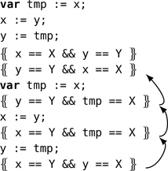

图2.0。 为证明这个程序片段交换x和y的值，图中从期望的后置条件开始反向推理。随后需要证明第一个注解蕴含第二个注解。Figure 2.0. To prove that this program fragment swaps the values of x and y, the reasoning is shown backwards from the desired postcondition. One then has to show that the first annotation implies the second.

为了规定我们预期这个程序做什么，需要在后置条件中能够引用x和y的初始值。使用Hoare三元组时，可以通过引入*逻辑变量*来实现，即在证明中代表某些值、但不能在程序中使用的变量。以X和Y作为逻辑变量，写成To specify what we expect this program to do, we need a way in the postcondition to refer to the initial values of x and y. When we use Hoare triples, this feat is accomplished by introducing *logical variables*, that is, variables that stand for some values in our proof, but that cannot be used in the program. Using X and Y as logical variables, we write

{{ x == X && y == Y }}

**var** tmp := x;

x := y;

y := tmp;

{{ x == Y && y == X }}

这个程序由顺序组合的三条语句构成。要计算一列语句的最弱前置条件，只需逐条计算，如以下串接的Hoare三元组所示：This program consists of three statements, sequentially composed. To compute weakest preconditions for a sequence of statements, we simply do them one at the time, as is suggested by the following chaining sequence of Hoare triples:

{{ x == X && y == Y }}

{{ ? }}

**var** tmp := x;

{{ ? }}

x := y;

{{ ? }}

y := tmp;

{{ x == Y && y == X }}

在这一序列中，我们打算用最弱前置条件计算各问号处的谓词。计算完成后，第一个问号就被替换为整个语句序列的最弱前置条件。然后，需要证明给定前置条件蕴含这个最弱前置条件。开始吧：从后向前，一次处理一条语句，见图2.0。In this sequence, we intend to use weakest preconditions to compute predicates for the question marks. When we are done, the first question mark will have been replaced by the weakest precondition of the sequence of statements. We then need to prove that the given precondition implies the weakest precondition. Here we go—one at a time, from back to front, see Figure 2.0.

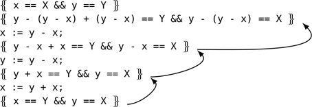

图2.1。 用于证明这个整数交换程序正确性的后向推理。Figure 2.1. Backward reasoning for proving the correctness of this program for swapping integers.

要得到这些中间公式，只需应用计算最弱前置条件的步骤。这就像做竖式乘法：系统地应用学过的步骤。接下来，需要证明逻辑蕴含To come up with these intermediate formulas, we just apply the recipe for computing weakest preconditions. It's like when we do long multiplication—we systematically apply the steps we've learned. Next, we need to do a proof of the logical implication

x == X && y == Y ==> y == Y && x == X

这里，蕴含显然成立。因此，我们已经证明上面的程序确实交换了x和y。In this case, the implication holds trivially. So, we have proved that the program above does swap x and y.

### 2.3.1. 记录程序证明的一种记法2.3.1. A notation for program-proof bookkeeping

再做一次验证程序正确交换数值的练习，但换一个程序。这次，假定x和y存储的是整数值：Let's repeat the exercise of verifying that a program correctly swaps, but for a different program. This time, we assume x and y to hold integer values:

{{ x == X && y == Y }}

x := y - x;

y := y - x;

x := y + x;

{{ x == Y && y == X }}

构造最弱前置条件，得到图2.1所示的结果。Constructing weakest preconditions, we get what is shown in Figure 2.1.

按箭头指示的顺序填入缺失部分时，我们所做的只是依照构造最弱前置条件的步骤进行替换。现在，得到一项证明义务：Filling in the missing parts in the order suggested by the arrows, all we did was perform substitutions according to the recipe for constructing weakest preconditions. Now, we have a proof obligation:

x == X && y == Y

==>

y - (y - x) + (y - x) == Y && y - (y - x) == X

经过一些算术化简，可以看出这一蕴含成立，因此程序正确地完成交换。After some arithmetic simplifications, we see that this implication holds, so the program correctly swaps.

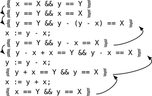

图2.2。 这个程序片段中的连续注解展示了公式的化简。每个此类注解中的公式都蕴含下一个注解中的公式。我觉得，这些化简沿正向（以蕴含相连接）阅读最容易理解。相比之下，程序语句前后的注解则按箭头所示，反向（使用最弱前置条件）构造。Figure 2.2. Consecutive annotations in this program fragment show simplifications of the formulas. The formula in one such annotation implies the formula in the next annotation. I find such simplifications easiest to read in the forward direction (connected by implication). In contrast, annotations around a program statement are constructed backwards (using weakest preconditions) as shown by the arrows.

像刚才那样构造最弱前置条件时，边推导边化简公式，而不是到最后才化简，会很有帮助。一种方便的记法是：反向推导时，在刚写下的公式上一行写出化简后的公式。如果进行多次化简，就可以上下写出多个公式。继续反向推导时，如果愿意，也可以加强公式。（小心！一个常见错误是在反向推导时*削弱*公式。这是不允许的，因为那样得不到证明。）最后，推导中就显示出由公式和程序语句构成的序列。对于每一对连续公式，必须证明前者蕴含后者；每条程序语句与其前后的两个公式，则必须构成有效的Hoare三元组。When we construct weakest preconditions like we did, it helps to simplify our formulas as we go along, rather than doing so only at the end. A convenient notation for this is to, working backward, write the simplified formula on the line above the one we just wrote. If we perform several simplifications, we can write several formulas above each other. If we want to, we are also allowed to strengthen the formula as we continue working backward. (Beware! A common mistake is to *weaken* the formula as you go backward. This is not allowed, because it will not give you a proof.) In the end, our derivation shows a sequence of formulas of program statements. For every pair of consecutive formulas, we need to prove that the former implies the latter, and every program statement between two formulas must be a valid Hoare triple.

图2.2按刚才所述，展示了前一个程序及其中间化简步骤。右侧箭头表示最弱前置条件的构造，因此构成有效的Hoare三元组。左侧箭头连接连续注解。它们可以反向构造，作为加强步骤，但许多人更习惯正向将其作为蕴含来检查。因此，我把左侧箭头画成正向。Figure 2.2 shows the previous program with intermediate simplifications, as just described. The arrows on the right show constructions of weakest preconditions, thus forming valid Hoare triples. The arrows on the left connect consecutive annotations. These may be constructed in the backward direction as strengthenings, but many people are more conditioned to check them as implications in the forward direction. Therefore, I'm showing the arrows on the left in the forward direction.

## 习题2.9。Exercise 2.9.

验证以下程序正确完成交换，其中^表示异或：Verify that the following program correctly swaps, where ^ denotes xor:

x := x ^ y;

y := x ^ y;

x := x ^ y;

可以使用异或的交换律和结合律，以及性质x ^ x == 0和x ^ 0 == x。You can use the commutativity and associativity of xor, as well as the properties x ^ x == 0 and x ^ 0 == x.

## 习题2.10。Exercise 2.10.

找出以下证明尝试中的错误：Find the error in the following proof attempt:

{{ x == 0 }}

{{ x == 0 && y == 6 }}

x := x + 2

{{ x == 2 && y == 6 }}

{{ x + y == 8 }}

y := x + y

{{ y == 8 }}

### 2.3.2. 同时赋值2.3.2. Simultaneous assignments

有些语言允许在一条语句中给多个变量赋值。这称为*同时赋值*。例如，Some languages allow several variables to be assigned in one statement. This is called *simultaneous assignment*. For example,

x, y := 10, 3;

将x设为10，同时将y设为3。再例如，sets x to 10 and, at the same time, sets y to 3. As another example,

x, y := x + y, x - y;

先计算x与y之和以及x与y之差，再分别将x和y更新为这两个结果。注意，在给任何变量赋值之前，会先计算所有右侧表达式。这就是赋值具有“同时性”的原因，也是它与两条赋值的*顺序组合*的区别：computes the sum of x and y and the difference between x and y, and then updates x and y to these, respectively. Note that all of the right-hand sides are computed before any variable is assigned. This is what makes the assignment “simultaneous”, and it is what distinguishes it from a *sequence* of two assignments:

x := x + y; y := x - y;

同时赋值的语义并不比单变量赋值更难。只需要让最弱前置条件中的替换也同时发生。更确切地说，要使赋值x, y := E, F确立条件Q，在赋值前需要的条件是Q[x, y := E, F]，即在Q中同时用E替换x，用F替换y。The semantics of simultaneous assignment is no more diﬃcult than an assignment to a single variable. All we need is for the weakest-precondition substitution to happen simultaneously as well. More precisely, for an assignment x, y := E, F to establish a condition Q, the condition we need before the assignment is Q[x, y := E, F], that is, Q in which we simultaneously substitute E for x and F for y.

同时赋值使交换两个变量值的程序变得简单得不能再简单：x, y := y, x。其证明如下：Simultaneous assignment gives us a ridiculously easy way to write a program for swapping the values of two variables: x, y := y, x. Here is its proof:

{{ x == X && y == Y }}

{{ y == Y && x == X }}

x, y := y, x

{{ x == Y && y == X }}

## 习题2.11。Exercise 2.11.

填入以下Hoare三元组中的问号。化简通过计算最弱前置条件得到的公式。Fill in the question marks in the following Hoare triples. Simplify the formulas you obtain by computing weakest preconditions.

| a) | {{ ? }} x, y := 6, 7 {{ x < 10 && y <= z }} |
| --- | --- |
| b) | {{ ? }} x, y := x + 1, 2 * x {{ y - x == 3 }} |
| c) | {{ ? }} x := x + 1; y := 2 * x {{ y - x == 3 }} |

### 2.3.3. 变量引入2.3.3. Variable introduction

局部变量用**var**语句引入。通常，我们将它与赋值一起使用，例如第2.3.0节中的**var** tmp := x。目前在处理语义时，我忽略了实际的变量引入（即“**var**”部分），而集中于赋值。但变量引入也有语义。为了讨论它，应当将**var**与语法上写在一起的初始赋值分开考虑。也就是说，**var** tmp := x实际上是两条语句：Local variables are introduced with the **var** statement. Most often, we use it together with an assignment, like **var** tmp := x in Section 2.3.0. So far in treating the semantics, I have ignored the actual variable introduction (that is, the “**var**” part) and focused on the assignment. But variable introduction also has semantics. To talk about it, we should think of **var** as being separate from any initial assignment that shares the syntax. That is, **var** tmp := x is really two statements:

**var** tmp;

tmp := x;

每个变量都有类型，但局部变量的类型通常由系统推断，因此未必会在程序中显式出现。Every variable has a type, but the type of a local variable is usually inferred, so you may not see it explicitly in the program.

语句**var** x引入x，但对x的初始值不作任何承诺（只保证x具有其类型的某个值）。因此，要使**var** x确立谓词Q，变量引入之前需要的条件是：Q对x的所有值都成立。写成Hoare三元组，就是The statement **var** x introduces x, but does not promise anything about the initial value of x (other than that x will have some value of its type). Thus, in order for **var** x to establish a predicate Q, what we need before the variable introduction is that Q hold for all values of x. Written as a Hoare triple, we have

{{ **forall** x :: Q }} **var** x {{ Q }}

例如，对于整数变量x，假设Q为0 <= x < 100。那么，以下是一个有效的Hoare三元组：For example, for an integer variable x, suppose Q is 0 <= x < 100. Then, the following is a valid Hoare triple:

{{ **forall** x :: 0 <= x < 100 }} **var** x {{ 0 <= x < 100 }}

条件**forall** x :: 0 <= x < 100就是**false**，因为条件0 <= x < 100并非对所有整数都成立（例如102）。所以，这说明**var** x完全不能保证x最终落在0到100的范围内。The condition **forall** x :: 0 <= x < 100 is just **false**, because the condition 0 <= x < 100 does not hold universally of all integers (case in point: 102). So, this says that **var** x in no way guarantees that x will end up in the range from 0 to 100.

一般而言，如果Q以任何非平凡的方式提及x，那么就无法证明**var** x会确立Q。但不要因此以为变量引入从来没有用处：其语义只是恰当地刻画了未初始化变量可以具有任意值这一事实。如果希望依赖变量的取值，最好先给它赋值。Generally, if Q mentions x in any nontrivial way, then there's no way to prove that **var** x will establish Q. But don't go thinking that variable introduction is never useful—the semantics just properly captures the fact that uninitialized variables can have any value. If we want to depend on what value the variable has, then we had better first assign to it.

举个例子，证明可以引入一个局部变量，暂存打算赋给另一个变量的值。从赋值的最弱前置条件可知，只要语句从Q[x:= E]开始，x := E就会确立Q。那么，**var** tmp := E; x := tmp何时会确立Q呢？其中tmp是在E和Q中都未使用的变量。以下Hoare三元组链表明，答案是Q[x := E]，与直接赋值x := E一样。As an example, let's prove that we can introduce a local variable to temporarily store a value we intend to assign to another variable. We know from the weakest precondition of assignment that x := E will establish Q provided the statement is started in Q[x:= E]. When will **var** tmp := E; x := tmp establish Q, where tmp is a variable that is not used in either E or Q? The following chain of Hoare triples show the answer to be Q[x := E], just as for the direct assignment x := E.

{{ Q[x := E] }}

{{ **forall** tmp :: Q[x := E] }}

**var** tmp

{{ Q[x := E] }}

{{ Q[x := tmp][tmp := E] }}

tmp := E

{{ Q[x := tmp] }}

x := tmp

{{ Q }}

照例，上面的各行最好自下而上阅读。从Q[x := tmp][tmp := E]化简为Q[x := E]，依据是tmp不在Q中出现。从As usual, the lines above are best read from bottom to top. The simplification from Q[x := tmp][tmp := E] to Q[x := E] is justified by the fact that tmp does not occur in Q. The simplification from

**forall** tmp :: Q[x := E]

化简为Q[x := E]，依据是tmp不在表达式Q[x := E]中出现。to Q[x := E] is justified by the fact that tmp does not occur in the expression Q[x := E].

## 习题2.12。Exercise 2.12.

下面是一个不依赖x初始值的例子。证明：Here is an example that does not depend on the initial value of x. Prove:

{{ **true** }} **var** x; x := x * x {{ 0 <= x }}

### 2.3.4. 复杂的那个2.3.4. The complicated one

好吧，尽管不会经常使用，但不向你展示如何计算赋值的最强后置条件也不太公平。它不像最弱前置条件那样只是简单替换。它很复杂。做好准备。Okay, it wouldn't be fair not to show you how to compute the strongest postcondition for an assignment, even if we won't use it much. It is not the simple substitution we had for weakest preconditions. It's complicated. Brace yourself.

为了说明最强后置条件的计算步骤为何如此，考虑以下看似无害的Hoare三元组：To motivate the recipe for strongest postconditions, consider the following, innocent-looking Hoare triple:

{{ w < x < y }} x := 100 {{ ? }}

显然，x == 100是一个后置条件，但它是最强的吗？条件w < x < y不再成立，因为赋值覆盖了x原来的值。然而，在后状态中，存在某个值x<sub>0</sub>（即x在前状态中的值），使w < x<sub>0</sub> < y成立。因此，能为问号写下的最精确条件是：It's clear that x == 100 is a postcondition, but is it the strongest? The condition w < x < y no longer holds, because the assignment overwrites the previous value of x. However, in the post-state, there exists some value x<sub>0</sub> (namely, the value of x in the pre-state) for which w < x<sub>0</sub> < y holds. So, the most precise condition we can write for the question mark is:

**exists** x<sub>0</sub> :: w < x<sub>0</sub> < y && x == 100

由于涉及的变量都是整数，该公式在逻辑上等价于Since the variables involved are integers, this formula is logically equivalent to

w + 1 < y && x == 100

一般而言，赋值右侧也可能提及x，因此那里也需要使用x<sub>0</sub>。所以，结果如下：In general, the right-hand side of the assignment may also mention x, so we'll need to use the x<sub>0</sub> there, too. So here it is:

{{ P }} x := E {{ **exists** x<sub>0</sub> :: P[x := x<sub>0</sub>] && x == E[x := x<sub>0</sub>] }}

你是不是很庆幸问了这个问题？Aren't you glad you asked?

## 习题2.13。Exercise 2.13.

通过计算最强后置条件，替换以下Hoare三元组中的?。如有可能，化简每个公式。Replace the ? in the following Hoare triples by computing strongest postconditions. In each case, simplify the formula, if possible.

| a) | {{ y == 10 }} x := 12 {{ ? }} |
| --- | --- |
| b) | {{ 98 <= y }} x := x + 1 {{ ? }} |
| c) | {{ 98 <= x }} x := x + 1 {{ ? }} |
| d) | {{ 98 <= y < x }} x := 3 * y + x {{ ? }} |

## 习题2.14。Exercise 2.14.

使用最强后置条件，验证第2.3.0节中各个交换程序的正确性。Verify the correctness of the various swap programs in Section 2.3.0 using strongest postconditions.

## 2.4. 𝒲𝒫与𝒮𝒫2.4. 𝒲𝒫 and 𝒮𝒫

引入一些记法，可以节省很多文字。假设S是一条语句。对于S前状态上的任意谓词P，定义𝒮𝒫〚S, P⟧表示S相对于P的最强后置条件。类似地，对于S后状态上的任意谓词Q，定义𝒲𝒫〚S, Q⟧表示S相对于Q的最弱前置条件。We can save many words by introducing some notation. Suppose S is a statement. Then, for any predicate P on the pre-state of S, let's define 𝒮𝒫〚S, P⟧ to denote the strongest postcondition of S with respect to P. Similarly, for any predicate Q on the post-state of S, let's define 𝒲𝒫〚S, Q⟧ to denote the weakest precondition of S with respect to Q.

### 2.4.0. 后向推理2.4.0. Working backward

使用这种记法，赋值的语义定义如下：Using this notation, the semantics of assignment is defined as follows:

𝒲𝒫〚x := E, Q⟧ = Q[x := E]

𝒮𝒫〚x := E, P⟧ = **exists** x<sub>0</sub> :: P[x := x<sub>0</sub>] && x == E[x := x<sub>0</sub>]

只要x、x<sub>0</sub>和E是长度相同的列表，这些𝒲𝒫和𝒮𝒫等式，就既适用于单变量赋值，也适用于多个变量的同时赋值。These 𝒲𝒫 and 𝒮𝒫 equations apply for assignments to one variable as well as simultaneous assignment to several variables, as long as x, x<sub>0</sub>, and E are lists of the same length.

跨越赋值语句进行*后向推理*非常有用，因为它能把赋值后希望成立的条件Q，转换为赋值前需要成立的条件。第2部分会经常使用这一步。It is very useful to *work backward* over an assignment statement, because it lets you convert a condition Q that you want to hold after the assignment into a condition that needs to hold prior to the assignment. I will make frequent use of this step in Part 2.

## 习题2.15。Exercise 2.15.

练习后向推理：计算以下程序相对于后置条件x + y <= 100的最弱前置条件。Practice working backward: Compute the weakest precondition of the following programs with respect to the postcondition x + y <= 100.

| a) x := 20 |  | b) x := x + 1 |
| --- | --- | --- |
| c) x := 2 * x |  | d) x := -x |
| e) x := y |  | f) x := x + y |
| g) x := y - x |  | h) x := x - y |
| i) z := x + y |  |  |

化简每个答案。In each case, simplify your answer.

## 习题2.16。Exercise 2.16.

计算以下程序相对于前置条件x + y <= 100的最强后置条件。Compute the strongest postcondition of the following programs with respect to the precondition x + y <= 100.

| a) x := 5 |  | b) x := x + 1 |
| --- | --- | --- |
| c) x := 2 * y |  | d) z := x + y |

化简每个答案。In each case, simplify your answer.

### 2.4.1. 局部变量2.4.1. Local variables

在第2.3.3节中，我用最弱前置条件介绍了**var**的语义。下面同时以𝒲𝒫和𝒮𝒫给出其语义：In Section 2.3.3, I presented the semantics of **var** in terms of weakest preconditions. Here is its semantics in terms of both 𝒲𝒫 and 𝒮𝒫:

𝒲𝒫〚**var** x, Q⟧ = **forall** x :: Q

𝒮𝒫〚**var** x, P⟧ = **exists** x :: P

## 习题2.17。Exercise 2.17.

计算Compute

| a) | 𝒲𝒫〚**var** x, x <= 100⟧ |
| --- | --- |
| b) | 𝒮𝒫〚**var** x, x <= 100⟧ |

化简每个答案。In each case, simplify your answer.

## 2.5. 条件控制流2.5. Conditional Control Flow

为了了解Floyd逻辑如何处理如下条件语句，To learn what Floyd logic says about conditional statements, like

**if** B { S } **else** { T }

画出控制流图会很有启发。这里用U、V、W、X、Y和Z，表示条件语句及其两个子语句S和T开始和结束处的谓词：it is instructive to draw the control-flow graph. Here, I'm using U, V, W, X, Y, and Z to denote predicates at the beginning and end of the conditional statement and of its two substatements, S and T:

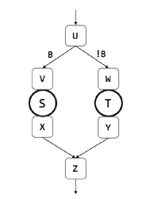

Floyd逻辑告诉我们，如果以下公式和Hoare三元组有效，那么这个带注解的程序就正确：Floyd logic tells us that this decorated program is correct if the following are valid formulas and valid Hoare triples:

- U && B ==> V
- U && !B ==> W
- {{ V }} S {{ X }}
- {{ W }} T {{ Y }}
- X ==> Z
- Y ==> Z

如果计算最强后置条件，就If we're computing strongest postconditions, then we

- 将V设为U && B，将W设为U && !B，set V to U && B and set W to U && !B,
- 将X计算为V,S的最强后置条件，将Y计算为W,T的最强后置条件，并且compute X as the strongest postcondition for V,S and compute Y as the strongest postcondition for W,T, and
- 将Z设为X || Y。set Z to X || Y.

以图形表示，就是这里左侧所示的图：Pictorially, we have the diagram shown here to the left:

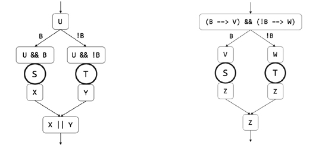

要计算最弱前置条件，则改为To compute weakest preconditions, we instead

- 将X和Y都设为Z，set both X and Y to Z,
- 将V计算为S,X的最弱前置条件，将W计算为T,Y的最弱前置条件，并且compute V as the weakest precondition of S,X and compute W as the weakest pre-condition of T,Y, and
- 将U设为(B ==> V) && (!B ==> W)。set U to (B ==> V) && (!B ==> W).

以图形表示，就是上面右侧所示的图。Pictorially, we have the diagram shown above to the right.

不论如何得到图中的中间谓词，都应观察沿控制流图的边前进时，无论正向还是反向，谓词是如何变换的。Regardless of how you come up with the intermediate predicates in these diagrams, what you should observe is how the predicates are transformed as you follow—either forwards or backwards—the edges of the control-flow graph.

下面是相同的流程图，但在图中标出了𝒮𝒫和𝒲𝒫：Here are the same flow diagrams, but showing 𝒮𝒫 and 𝒲𝒫 in the diagrams:

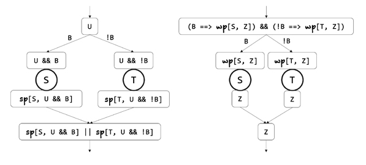

## 习题2.18。Exercise 2.18.

(a) 为以下条件语句绘制与上面类似的带注解流程图：(a) Draw a decorated flow diagram as the ones above for the conditional statement

**if** x < 3 { x, y := x + 1, 10; } **else** { y := x; }

(b) 沿正向，以x + y == 100为前置条件（即U），填入其余方框中的公式。(c) 沿反向，以x + y == 100为后置条件（即Z），填入其余方框中的公式。(b) In the forward direction and using x + y == 100 as the precondition (that is, as U), fill in the formulas in the remaining boxes. (c) In the backward direction and using x + y == 100 as the postcondition (that is, as Z), fill in the formulas in the remaining boxes.

### 2.5.0. 只要公式，女士2.5.0. Just the formulas, ma’am

只用公式、不用图来写，以𝒮𝒫和𝒲𝒫表达的if语句含义如下：Written with just formulas—no diagrams—the meaning of if statements in terms of 𝒮𝒫 and 𝒲𝒫 is:

𝒮𝒫〚**if** B { S } **else** { T }, P⟧ =

𝒮𝒫〚S, P && B⟧ || 𝒮𝒫〚T, P && !B⟧

𝒲𝒫〚**if** B { S } **else** { T }, Q⟧ =

(B ==> 𝒲𝒫〚S, Q⟧) && (!B ==> 𝒲𝒫〚T, Q⟧)

## 习题2.19。Exercise 2.19.

假设已知x < 100在以下语句之前成立：Suppose x < 100 is known to hold before the statement

**if** x < 20 { y := 3; } **else** { y := 2; }

那么，在该语句之后，你所知道的最强条件是什么？换句话说，计算该语句相对于x < 100的最强后置条件。计算后化简该条件。then what is the strongest condition you know after the statement? In other words, compute the strongest postcondition of the statement with respect to x < 100. Simplify the condition after you have computed it.

## 习题2.20。Exercise 2.20.

假设希望x + y == 22在以下语句之后成立：Suppose you want x + y == 22 to hold after the statement

**if** x < 20 { y := 3; } **else** { y := 2; }

那么，可以从哪些状态开始执行该语句？换句话说，计算该语句相对于x + y == 22的最弱前置条件。计算后化简该条件。then in which states can you start the statement? In other words, compute the weakest precondition of the statement with respect to x + y == 22. Simplify the condition after you have computed it.

## 习题2.21。Exercise 2.21.

计算以下语句相对于y < 10的最弱前置条件。化简该条件。Compute the weakest precondition for the following statement with respect to y < 10. Simplify the condition.

**if** x < 8 {

**if** x == 5 {

y := 10;

} **else** {

y := 2;

}

} **else** {

y := 0;

}

## 习题2.22。Exercise 2.22.

计算以下语句相对于y % 2 == 0（即“y为偶数”）的最弱前置条件。化简该条件。Compute the weakest precondition for the following statement with respect to y % 2 == 0 (that is, “y is even”). Simplify the condition.

**if** x < 10 {

**if** x < 20 { y := 1; } **else** { y := 2; }

} **else** {

y := 4;

}

## 习题2.23。Exercise 2.23.

计算以下语句相对于y % 2 == 0（即“y为偶数”）的最弱前置条件。化简该条件。Compute the weakest precondition for the following statement with respect to y % 2 == 0 (that is, “y is even”). Simplify the condition.

**if** x < 8 {

**if** x < 4 { x := x + 1; } **else** { y := 2; }

} **else** {

**if** x < 32 { y := 1; } **else** { }

}

## 习题2.24。Exercise 2.24.

确定以下程序在何种情况下会确立0 <= y < 100。如果你已开始掌握如何计算最弱前置条件，试着在头脑中完成计算。写下所得答案，再写出完整的𝒲𝒫计算过程，检查答案是否正确。Determine under which circumstances the following program establishes 0 <= y < 100. If you're starting to get a hang of how to compute weakest preconditions, try to do the computation in your head. Write down the answer you come up with, and then write out the full 𝒲𝒫 computations to check that you got the right answer.

**if** x < 34 {

**if** x == 2 { y := x + 1; } **else** { y := 233; }

} **else** {

**if** x < 55 { y := 21; } **else** { y := 144; }

}

## 2.6. 顺序组合2.6. Sequential Composition

组合两条语句的另一种方式，是让一条接在另一条之后。这个简单思想有个多音节的名字：*顺序组合*。对于语句S和T，可以通过写出两个相互重叠的Hoare三元组，表达S;T的Floyd逻辑语义：Another way to compose two statements is to follow one by the other. This simple idea goes by the multi-syllable name *sequential composition*. For statements S and T, we can convey the Floyd logic semantics of S;T by writing two overlapping Hoare triples

{{ P }} S {{ Q }} T {{ R }}

如果以下两个单独的Hoare三元组有效，上面的组合就有效：This is valid if the following two individual Hoare triples are valid:

- {{ P }} S {{ Q }}
- {{ Q }} T {{ R }}

没有必要涉及谓词Q，因为将Q设为𝒮𝒫〚S, P⟧或𝒲𝒫〚T, R⟧都不失一般性。换句话说，可以直接用最强后置条件或最弱前置条件定义以下Hoare三元组的有效性：There's no reason we have to involve the predicate Q, because there is no loss in generality by setting Q to either 𝒮𝒫〚S, P⟧ or 𝒲𝒫〚T, R⟧. In other words, we can directly define the validity of the Hoare triple

{{ P }} S;T {{ R }}

以公式表示，得到in terms of strongest postconditions or weakest preconditions. In formulas, we have

𝒮𝒫〚S;T, P⟧ = 𝒮𝒫〚T, 𝒮𝒫[S, P⟧ ⟧

𝒲𝒫〚S;T, R⟧ = 𝒲𝒫〚S, 𝒲𝒫〚T, R⟧ ⟧

注意，两个右侧中的组合方向相反：𝒮𝒫从P正向计算，𝒲𝒫则从R反向计算。Notice that the compositions in these two right-hand sides go in opposite directions—𝒮𝒫 is computed forwards from P and 𝒲𝒫 is computed backward from R.

## 习题2.25。Exercise 2.25.

以下哪些Hoare三元组组合有效？Which of the following Hoare-triple combinations are valid?

| a) | {{ 0 <= x }} x := x + 1 {{ -2 <= x }} y := 0 {{ -10 <= x }} |
| --- | --- |
| b) | {{ 0 <= x }} x := x + 1 {{ **true** }} x := x + 1 {{ 2 <= x }} |
| c) | {{ 0 <= x }} x := x + 1; x := x + 1 {{ 2 <= x }} |
| d) | {{ 0 <= x }} x := 3 * x; x := x + 1 {{ 3 <= x }} |
| e) | {{ x < 2 }} y := x + 5; x := 2 * x {{ x < y }} |

## 习题2.26。Exercise 2.26.

练习跨越多条赋值语句进行后向推理。对于以下程序，计算相对于x + y <= 100的𝒲𝒫：Practice working backward over several assignment statements. Compute 𝒲𝒫 with respect to x + y <= 100 for the following programs:

| a) | x := x + 1; y := x + y |
| --- | --- |
| b) | y := x + y; x := x + 1 |
| c) | x, y := x + 1, x + y |

## 习题2.27。Exercise 2.27.

对于以下程序，计算相对于x + y <= 100的𝒮𝒫：Compute 𝒮𝒫 with respect to x + y <= 100 for the following programs:

| a) | x := x + 1; y := x + y |
| --- | --- |
| b) | y := x + y; x := x + 1 |
| c) | x, y := x + 1, x + y |

## 习题2.28。Exercise 2.28.

计算以下语句相对于谓词x + y < 100的最强后置条件和最弱前置条件。化简这些谓词。Compute the strongest postcondition and weakest precondition of the following statements, each with respect to the predicate x + y < 100. Simplify the predicates.

| a) | x := 32; y := 40 |
| --- | --- |
| b) | x := x + 2; y := y - 3 * x |

## 习题2.29。Exercise 2.29.

计算Compute

| a) | 𝒲𝒫[**var** x; x := 10, x <= 100] |
| --- | --- |
| b) | 𝒮𝒫[**var** x; x := 10, x <= 100] |

## 习题2.30。Exercise 2.30.

计算以下语句相对于谓词x < 10的最强后置条件和最弱前置条件：Compute the strongest postcondition and weakest precondition of the following statements, each with respect to the predicate x < 10:

**if** x % 2 == 0 { y := y + 3; } **else** { y := 4; }

**if** y < 10 { y := x + y; } **else** { x := 8; }

## 2.7. 方法调用与后置条件2.7. Method Calls and Postconditions

方法是不透明的。这意味着我们依据规约，而不是实现（方法体），对方法进行推理。再次考虑第1.4节中的Triple方法：Methods are opaque. This means we reason about them in terms of their specifications, not their implementations (their bodies). Consider our Triple method from Section 1.4 again:

**method** Triple(x: **int**) **returns** (y: **int**)

**ensures** y == 3 * x

基本思想是，我们预期能够证明如下Hoare三元组：The basic idea is that we expect to be able to prove Hoare triples like

{{ **true** }} t := Triple(u + 3) {{ t == 3 * (u + 3) }}

（这*确实*符合你的预期，对吧？）为了精确表述，需要考虑几个细节。先从参数开始。(This *is* what you'd expect, right?) To make this precise, we need to consider several details. Let's start with the parameters.

### 2.7.0. 参数2.7.0. Parameters

为说明起见，使用以下调用：For illustration, let's use the call

t := Triple(u + 3)

规约使用形式参数x和y，而调用位置使用实际参数u + 3和t。我们必须以某种方式把它们联系起来。由于可能发生各种命名冲突，包括形式参数和实际参数名称重叠，首先要给形式参数赋予*全新*的名称。也就是说，将形式参数重命名为验证中尚未使用的名称。换一种说法，只要这些名称是本调用位置独有的，它们就是全新的。The specification uses the formal parameters x and y, whereas the call site uses the actual parameters u + 3 and t. Somehow, we must connect these. Because of various possible name clashes, including any overlap in the names of the formal and actual parameters, we start by giving the formal parameters *fresh* names. That is, we rename the formal parameters to names that are not already used in our verification. Stated in yet one more way, the names are fresh if they are unique to this call site.

这一步中，我把x重命名为x’，把y重命名为y’。采用这些全新名称，方法及其规约如下：For this step, I will rename x to x’ and y to y’. With these fresh names, the method and its specification look like this:

**method** Triple(x’: **int**) **returns** (y’: **int**)

**ensures** y’ == 3 * x’

现在，可以把调用的含义解释为一种顺序组合：先将实际输入参数赋给重新命名的形式输入参数，再将重新命名的形式输出参数赋给实际输出参数；其中重要的是，可以假定这些重新命名的变量之间满足后置条件所规定的关系。在本例中，这两次赋值是x’ := u + 3和t := y’，可以假定的关系是y’ == 3 * x’。The meaning of the call can now be explained as the sequential composition of first assigning the actual in-parameters to the freshly named formal in-parameters and then assigning the freshly named formal out-parameters to the actual out-parameters, where—importantly—we get to assume the relation between the freshly named variables entailed by the postconditions. For our example, these two assignments are x’ := u + 3 and t := y’, and the relation we get to assume is y’ == 3 * x’.

### 2.7.1. 假设2.7.1. Assumptions

为了使表述更精确，如果有一条引入假设的程序语句，会很方便。为此，对布尔表达式E，定义语句**assume** E。对于任意前状态谓词P和后状态谓词Q，**assume**的语义由以下两个等式给出：To make things more precise, it would be convenient to have a program statement that introduced an assumption. For this purpose, let me define a statement **assume** E for a boolean expression E. For any pre-state predicate P and post-state predicate Q, the semantics of **assume** is given by the following two equations:

𝒮𝒫〚**assume** E, P⟧ = P && E

𝒲𝒫〚**assume** E, Q⟧ = E ==> Q

第一个等式表示，如果从满足P的状态开始执行**assume** E，那么之后可以假定P和E都成立。第二个等式表示，如果想证明Q在**assume** E之后成立，那么只需在该语句之前证明：在假设E下，Q成立。The first of these equations says that if you start **assume** E in a state satisfying P, then you get to assume that both P and E hold afterwards. The second equation says that if you want to prove Q to hold after **assume** E, then it suﬃces to prove, before the statement, that Q holds under the assumption E.

**assume**语句是虚构的。也就是说，它不是编译器能够处理的语句。毕竟，它引入一个假设，就像让愿望成真一样。不过，如果仅仅把这条虚构语句理解为“哦，在这里，我显然可以假定条件E成立”，那么**assume**语句作为定义非虚构语句语义的原语，就非常方便。例如，调用语句。The **assume** statement is fictitious. That is, it is not a statement that a compiler could handle. After all, it introduces an assumption, much like making a wish come true. Nevertheless, if you just think of the fictitious statement as “oh, at this point, I apparently get to assume that condition E holds”, then this **assume** statement is quite handy as a primitive in defining the semantics of non-fictitious statements. Like the call statement.

### 2.7.2. 带后置条件的方法调用语义2.7.2. Semantics of method call with a postcondition

利用重命名和假设，可以定义示例调用的语义。上面，我们已将Triple的形式参数重命名为全新名称。接下来，由以下程序片段给出调用的语义：Using renaming and an assumption, we can define the semantics of our illustrative call. Above, we already freshly renamed the formal parameters of Triple. Next, the semantics of the call is given by the following program snippet:

**var** x’, y’;

x’ := u + 3;

**assume** y’ == 3 * x’;

t := y’

换句话说，我的意思是，对调用In other words, I'm saying that you reason about the call

t := Triple(u + 3)

进行推理的方式，与对这四条语句推理相同。in the same way as you reason about these four statements.

因此，以最弱前置条件表示，对于任意谓词Q，有In terms of weakest preconditions, we thus have, for any predicate Q,

𝒲𝒫〚t := Triple(u + 3), Q⟧

= { *definition of a call in terms of the four statements* }

𝒲𝒫〚**var** x’,y’; x’ := u + 3; **assume** y’ == 3 * x’; t := y’, Q⟧

= { *definition of* 𝒲𝒫 *for* ; }

𝒲𝒫〚**var** x’,y’, 𝒲𝒫〚x’ := u + 3,

𝒲𝒫〚**assume** y’ == 3 * x’, 𝒲𝒫〚t := y’, Q⟧ ⟧ ⟧ ⟧

= { *definition of* 𝒲𝒫 *for* := *and* **assume** *and* **var** }

**forall** x’, y’ :: (y’ == 3 * x’ ==> Q[t := y’])[x’ := u + 3]

= { *apply the substitution for* x’ }

**forall** x’, y’ :: y’ == 3 * (u + 3) ==> Q[t := y’]

= { x’ *is not used* }

**forall** y’ :: y’ == 3 * (u + 3) ==> Q[t := y’]

= { *logic* }

Q[t := y’][y’ := 3 * (u + 3)]

= { *apply substitution for* y’ }

Q[t := 3 * (u + 3)]

来试一试。例如，取Q为t == 54。也就是说，如果希望调用t := Triple(u + 3)确立t == 54，那么调用之前需要成立什么条件？Let's try this out. As an example, take Q to be t == 54. That is, if we want the call t := Triple(u + 3) to establish t == 54, then what needs to holds before we make the call?

𝒲𝒫〚t := Triple(u + 3), t == 54⟧

= { 𝒲𝒫 *of call, see above* }

(t == 54)[t := 3 * (u + 3)]

= { *substitutions* }

3 * (u + 3) == 54

= { *arithmetic* }

u == 15

所以，如果希望t := Triple(u + 3)确立t == 54，就必须确保在u == 15时进行调用。这符合我们对调用及其规约的理解，因为如果u为15，那么u + 3为18，于是Triple返回54。So, if we want t := Triple(u + 3) to establish t == 54, we must make sure to make the call when u == 15. This matches our understanding of the call and its specification, because if u is 15, then u + 3 is 18, and then Triple returns 54.

更一般地，对于方法More generally, for a method

**method** M(x: X) **returns** (y: Y)

**ensures** R

对M的调用的语义为the semantics of a call to M is

𝒲𝒫〚t := M(E), Q⟧ =

**forall** x’, y’ :: (R[x,y := x’,y’] ==> Q[t := y’])[x’ := E]

其中，x’和y’是全新名称，Q是调用后状态上的任意谓词。注意，我在这个等式中直接包含了重命名，而不是先单独进行重命名步骤。由于x’是全新的，它不出现在Q中，因此可以通过分配替换操作来化简等式：where x’ and y’ are fresh names and Q is any predicate on the post-state of the call. Notice that I included the renaming in this equation, rather than first doing a renaming step. Since x’ is fresh, it does not occur in Q, so we can simplify the equation by distributing the substitutions:

𝒲𝒫〚t := M(E), Q⟧ =

**forall** y’ :: R[x,y := E,y’] ==> Q[t := y’]

上述内容适用于任意多个输入和输出参数。也就是说，x、y和t是变量列表，E是表达式列表时，同样适用（只要x与E长度相同，y与t长度相同，并且列表t中没有重复变量）。What I wrote applies to any number of in- and out-parameters. That is, it applies equally well if x, y, and t are lists of variables and E is a list of expressions (provided x and E have the same lengths, y and t have the same lengths, and there are no duplicates among the variables in the list t).

## 习题2.31。Exercise 2.31.

计算调用t := Abs(7 * u)相对于后置条件u < t的最弱前置条件，其中Abs定义如下：Compute the weakest precondition for a call t := Abs(7 * u) with respect to the postcondition u < t, where Abs is defined as follows:

**method** Abs(x: **int**) **returns** (y: **int**)

**ensures** 0 <= y && (x == y || x == -y)

化简答案。Simplify your answer.

## 习题2.32。Exercise 2.32.

计算调用t := Max(2 * u, u + 7)相对于后置条件t % 2 == 0的最弱前置条件，其中Max定义如下：Compute the weakest precondition for a call t := Max(2 * u, u + 7) with respect to the postcondition t % 2 == 0, where Max is defined as follows:

**method** Max(x: **int**, y: **int**) **returns** (m: **int**)

**ensures** m == x || m == y

**ensures** x <= m && y <= m

化简答案。Simplify your answer.

既然已经能用四条更基本的语句给出调用语义，调用的最强后置条件语义也就随之得到。对于示例中Triple调用前状态上的任意谓词P，有：Since we have a way to give the semantics of a call in terms of the four more primitive statements, the strongest-postcondition semantics of a call follows. For any predicate P on the pre-state of the illustrative call to Triple, we have:

𝒮𝒫〚t := Triple(u + 3), P⟧

= { *definition of a call in terms of the four statements* }

𝒮𝒫〚**var** x’,y’; x’ := u + 3; **assume** y’ == 3 * x’; t := y’, P⟧

= { *definition of 𝒮𝒫 for* ; }

𝒮𝒫〚**var** x’,y’, 𝒮𝒫〚t := y’,

𝒮𝒫[**assume** y’ == 3 * x’, 𝒮𝒫〚x’ := u + 3, P⟧ ⟧ ⟧ ⟧

= { *definition of 𝒮𝒫 for* :=*, simplifying since x’ is fresh* }

𝒮𝒫〚**var** x’,y’, 𝒮𝒫〚t := y’,

𝒮𝒫〚**assume** y’ == 3 * x’, P && x’ == u + 3⟧ ⟧ ⟧

= { *definition of* 𝒮𝒫 *for* **assume** }

𝒮𝒫〚**var** x’,y’, 𝒮𝒫〚t := y’,

P && x’ == u + 3 && y’ == 3 * x’⟧ ⟧

= { *definition of 𝒮𝒫 for* :=*, where* t<sub>0</sub> *is fresh* }

𝒮𝒫〚**var** x’,y’,

**exists** t<sub>0</sub> :: (P && x’ == u + 3 && y’ == 3 * x’)[t := t<sub>0</sub>] && t == y’⟧

= { *simplification* }

𝒮𝒫〚var x’,y’,

**exists** t<sub>0</sub> :: P**[**t := t<sub>0</sub>**]** && x’ == u + 3 && y’ == 3 * x’ && t == y’⟧

= { *definition of* 𝒮𝒫 *for* **var** }

**exists** x’, y’ :: **exists** t<sub>0</sub> ::

P[t := t<sub>0</sub>] && x’ == u + 3 && y’ == 3 * x’ && t == y’

= { *logic simplification for* x’ }

**exists** y’ :: **exists** t<sub>0</sub> ::

(P[t := t<sub>0</sub>] && y’ == 3 * x’ && t == y’)[x’ := u + 3]

= { *apply substitution for* x’ }

**exists** y’ :: **exists** t<sub>0</sub> ::

P[t := t<sub>0</sub>] && y’ == 3 * (u + 3) && t == y’

= { *logic simplification for* y’ }

(**exists** t<sub>0</sub> :: P[t := t<sub>0</sub>] && y’ == 3 * (u + 3))[y’ := t]

= { *apply substitution for* y’ }

**exists** t<sub>0</sub> :: P[t := t<sub>0</sub>] && t == 3 * (u + 3)

一般情况下，若M是上述带后置条件R的方法，则有In the general case where M is the method above with the postcondition R, we have

𝒮𝒫〚t := M(E), P⟧ =

**exists** t<sub>0</sub> :: P[t := t<sub>0</sub>] && R[x := E[t := t<sub>0</sub>]][y := t]

其中t<sub>0</sub>是全新名称。（不知道你怎样，我觉得最弱前置条件的表述，比这个最强后置条件的表述更容易理解。）where t<sub>0</sub> is fresh. (I don't know about you, but I find the weakest-precondition formulation easier to understand than this strongest-postcondition formulation.)

## 2.8. 断言语句2.8. Assert Statements

上面对方法调用的描述，只展示了后置条件。在讨论前置条件之前，我先定义**assert**语句的语义。In what I described above for method calls, I only showed postconditions. Before I cover preconditions, I will define the semantics of **assert** statements.

如果E成立，语句**assert** E就是空操作；否则，它使程序崩溃。因此，如果想证明条件Q在语句之后成立，就必须证明E和Q在语句之前都成立：E用于防止断言导致崩溃，Q则是因为断言不改变状态。这由以下𝒲𝒫等式刻画：The statement **assert** E is a no-op if E holds; otherwise, it crashes your program. So if you want to prove that a condition Q holds after the statement, then you must prove that both E and Q hold before it—E to prevent the assertion from crashing, and Q because the assertion doesn't change the state. This is captured in the following 𝒲𝒫 equation:

𝒲𝒫〚**assert** E, Q⟧ = E && Q

我们始终希望证明程序不会崩溃，因此**assert**语句的作用就是引入一项证明义务。We're always interested in proving our programs to be crash-free, so the effect of the **assert** statement is to introduce a proof obligation.

## 习题2.33。Exercise 2.33.

计算以下语句相对于后置条件x < 100的最弱前置条件。化简每个答案。Compute the weakest precondition of the following statements with respect to the postcondition x < 100. Simplify each answer.

| a) | **assert** y == 25 |
| --- | --- |
| b) | **assert** 0 <= x |
| c) | **assert** x < 200 |
| d) | **assert** x <= 100 |
| e) | **assert** 0 <= x < 100 |

### 2.8.0. 𝒮𝒫与𝒲𝒫的真正区别2.8.0. The real difference between 𝒮𝒫 and 𝒲𝒫

下面是**assert**的𝒮𝒫等式：Here is the 𝒮𝒫 equation for **assert**:

𝒮𝒫〚**assert** E, P⟧ = P && E

它表示，在语句不崩溃地执行之后，最多可以确定P和E都成立。It says that the most you can be sure of after a crash-free execution of the statement is that both P and E hold.

到目前为止，选择使用𝒮𝒫还是𝒲𝒫，似乎颇为随意，或许只是偏好问题。好吧，对于赋值语句，𝒮𝒫比𝒲𝒫更复杂，但𝒮𝒫与𝒲𝒫之间还有更深的区别吗？有，而**assert**语句就凸显了这一差别。Until now, the choice of using 𝒮𝒫 versus 𝒲𝒫 has seemed rather arbitrary, or perhaps simply a matter of taste. Okay, for assignment statements, 𝒮𝒫 is more complicated than 𝒲𝒫, but is there any deeper difference between 𝒮𝒫 and 𝒲𝒫? Yes, there is, and the **assert** statement brings out this difference.

如果考虑仅使用𝒮𝒫定义语句的形式化含义，那么对于上述**assert**的𝒮𝒫等式，你会产生两个问题：If you would consider defining the formal meaning of statements using just 𝒮𝒫, then you would find yourself with two questions about the 𝒮𝒫 equation for **assert** above:

1. 0. **assert** E在什么情况下崩溃？例如，如果E不成立，语句是否必然崩溃？更值得关心的是，如果E成立，能否保证语句*不*崩溃？0. Under what circumstances does **assert** E crash? For example, will the statement always crash if E does not hold? Of greater interest, can we be assured that the statement does *not* crash if E holds?
2. 1. 断言应当提供引入证明义务的方式，那么𝒮𝒫如何刻画E是一项证明义务这一事实？1. An assertion is supposed to give us a way to introduce a proof obligation, so how does 𝒮𝒫 capture the fact that E is a proof obligation?

问题0的答案是：𝒮𝒫*并不*说明语句何时可能崩溃。它只说明，*如果*语句*不*崩溃，那么我们知道之后什么成立。The answer to question 0 is that 𝒮𝒫 does *not* say when a statement can crash. It only says that *if* the statement does *not* crash, then we know what holds afterwards.

问题1的答案是：𝒮𝒫并未刻画这一点。也就是说，𝒮𝒫并不知晓证明义务。回看第2.7.1节，你可能惊讶地发现，对于**assert** E和**assume** E，𝒮𝒫是一样的。在那一节，我把**assume** E定义为引入假设的虚构语句。这个假设可以免费获得，就像一个愿望或白日梦，不涉及证明义务。相比之下，**assert** E的预期含义是引入证明义务：我们不只是想假定条件E成立，还想证明它确实成立。然而，𝒮𝒫〚**assert** E, P⟧与𝒮𝒫〚**assume** E, P⟧相同。两者都只说明：*倘若*语句不崩溃地终止，那么P && E在之后成立。The answer to question 1 is that 𝒮𝒫 does not. That is, 𝒮𝒫 is incognizant of proof obligations. If you look back to Section 2.7.1, you may be alarmed to find that 𝒮𝒫 is the same for **assert** E as it is for **assume** E. In that section, I had defined **assume** E as a fictitious statement that introduces an assumption. This assumption comes for free, like a wish or a pipe dream, and there is no proof obligation involved. In contrast, the intended meaning of **assert** E is to introduce a proof obligation—we're not just assuming the condition E to hold, but we also want to prove that it does hold. Yet, 𝒮𝒫〚**assert** E, P⟧ is the same as 𝒮𝒫〚**assume** E, P⟧. Both of these say that *in the event that* the statement terminates without crashing, then P && E holds afterwards.

## 习题2.34。Exercise 2.34.

假设不使用𝒲𝒫，而只用𝒮𝒫定义语句语义。那么，依据𝒮𝒫等式，你会认为一条**assert**语句可能降低你的《糖果传奇》分数吗？Suppose we didn't use 𝒲𝒫, but we defined the semantics of a statement in terms of 𝒮𝒫 alone. Then, according to the 𝒮𝒫 equation, would you say that an **assert** statement could lower your Candy Crush score?

总之，𝒮𝒫告诉我们语句不崩溃地执行之后能够断言的最强条件，却不说明语句在何种情况下*确实*不会崩溃。相比之下，𝒲𝒫告诉我们：从哪些前状态出发，能够保证语句不崩溃，并在所需状态终止。**assert**和**assume**语句凸显了这个区别：In conclusion, 𝒮𝒫 tells us the strongest thing we can say upon crash-free execution of a statement, but it does not tell us under which circumstances a statement *is* crash-free. In contrast, 𝒲𝒫 tells us the pre-states from which a statement is guaranteed to be crash-free and terminate in a state we'd like. The **assert** and **assume** statements highlight this difference:

𝒲𝒫〚**assert** E, Q⟧ = E && Q

𝒲𝒫〚**assume** E, Q⟧ = E ==> Q

𝒮𝒫〚**assert** E, P⟧ = P && E

𝒮𝒫〚**assume** E, P⟧ = P && E

这些𝒲𝒫等式表示，如果想在语句之后确立Q，那么对于**assert** E，必须证明E成立，*并且*证明Q成立；而对于**assume** E，从来不必证明E成立，但在证明Q时仍然可以假定E。𝒮𝒫等式则只说明，如果语句不崩溃地终止，那么P && E成立。These 𝒲𝒫 equations say that if we want to establish Q after the statement, then for **assert** E, we must prove that E holds *and* prove that Q holds, whereas for **assume** E, we never need to prove that E holds and we still get to assume E when proving Q. The 𝒮𝒫 equations just say that if the statements terminate without crashing, then P && E holds.

### 2.8.1. 非形式化解读2.8.1. An informal reading

**assert**和**assume**这两个语句名称并非偶然。选择它们，是为了让我们能够内化语句的含义。只要按以下方式理解，就可以不去记忆它们的数学定义（或者说，只要理解这些，就没必要纠缠于形式化细节）：The names of the statements **assert** and **assume** are not accidental. They have been chosen to let us internalize what the statements mean. You can forget the mathematical definitions for these statements if (or: there's no reason to get caught up in the formal details as long as) you understand the statements like this:

> 语句**assert** E表示：“在这个程序位置，我们断言E成立；也就是说，我们预期E成立，并且将证明它确实成立。”也可以说：“我们预期每当控制流到达这个程序位置时，E都成立，而且将证明对所有可能执行确实如此。”The statement **assert** E says “at this program point, we assert that E holds; that is, we expect that E holds and we're going to prove that it does”. Alternatively, “we expect that whenever control reaches this program point, E holds, and we're going to prove that this is indeed the case for all possible executions”.

> 语句**assume** E表示：“在这个程序位置，我们不知道E是否成立；但为了证明程序正确性，我们将假定E在这里确实成立。”也可以说：“运行程序而控制流到达这里时，E可能成立，也可能不成立；但就我们的证明而言，将忽略所有到达这里而E不成立的执行。”The statement **assume** E says “at this program point, we have no idea if E holds or not; nevertheless, for the purpose of proving the correctness of our program, we are going to assume that E does hold here”. Alternatively, “when you run the program and control reaches this point, E may or may not hold, but as far as our proof is concerned, we are going to ignore any execution that gets here and E does not hold”.

### 2.8.2. 用assume推理调用2.8.2. Using assume to reason about calls

为什么我敢像第2.7.2节那样，用**assume**定义调用的含义？如果**assume**使证明忽略某些执行，我们真的还在证明程序正确性吗？在这种情况下，是的，我们仍然在证明程序正确性，因为我们将确保没有任何执行被忽略。对于方法M的调用，我在调用位置使用**assume**语句，假定M的后置条件。对程序进行推理时，我们迟早要证明M实现的正确性。在那个证明中，会确保方法实现确立后置条件。这样，每次调用返回时，被调用方法的后置条件都成立。因此，最终并没有忽略任何执行。How come I dare use **assume** when defining the meaning of calls, as I did in Section 2.7.2? Are we really proving the correctness of our program if the **assume** causes the proof to ignore certain executions? In this case, yes, we are still proving the correctness of our program, because we are going to make sure that no executions are ignored. For a call to a method M, I used the **assume** statement at the call site to assume the post-condition of M. Sooner or later in the reasoning about our program, we're going to prove the correctness of the implementation of M. In that proof, we are going to ensure that the method implementation establishes the postcondition. In this way, it will always be the case that, when a call returns, the postcondition of the method called holds. So, no executions are ignored after all.

这就为在调用定义中使用**assume**提供了依据。This justifies the use of **assume** in the definition of a call.

## 2.9. 最弱宽松前置条件2.9. Weakest Liberal Preconditions

本书的目标，是使你理解如何对程序进行推理，从而能严密地向自己、另一位软件工程师、甚至机器解释程序为何正确。底层语义有一个优美的方面，对证明程序正确而言并非必需。本节将带你略加领略。它也解释了上面第2.8.0节讨论的𝒲𝒫与𝒮𝒫之别的一些神秘之处。如果对底层语义的这类讨论不感兴趣，可以跳过本节，直接继续第2.10节。My aim in this book is to equip you with an understanding of how to reason about your programs, so that you can rigorously explain (to yourself or to a fellow software engineer, or even to a machine) why a program is correct. There is a beautiful aspect of the underlying semantics that is not strictly needed to prove your programs correct. I'm going to give you a taste of that beautiful aspect in this section. It also explains some of the mystery surrounding the difference between 𝒲𝒫 and 𝒮𝒫 that I talked about above in Section 2.8.0. If you don't care for such discussions about the underlying semantics, you can skip this section and instead continue with Section 2.10.

### 2.9.0. 将证明义务的刻画分离出来2.9.0. Turning capturing proof obligations into a separate concern

在第2.8.0节中，我指出，𝒮𝒫不刻画确保无崩溃的证明义务，而𝒲𝒫会刻画。此外，从一开始就很清楚，𝒮𝒫沿程序正向进行，而𝒲𝒫沿反向进行。正向进行是否意味着不能谈论（保证无崩溃的）证明义务？In Section 2.8.0, I pointed out that 𝒮𝒫 does not capture the proof obligations that ensure crash freedom, whereas 𝒲𝒫 does. It has also been clear from the beginning that 𝒮𝒫 proceeds in the forward direction of a program, whereas 𝒲𝒫 proceeds in the backward direction. Does going forward mean that we cannot speak about (crash-freedom) proof obligations?

不，并非完全如此。可以在正向定义第二个语义函数，用它跟踪所有证明义务。（参见后面的习题2.35。）在反向，𝒲𝒫已经做了这件事。也就是说，𝒲𝒫在反向进行时，会携带遇到的全部证明义务。例如，No, not entirely. We could define a second semantic function in the forward direction, one that would keep track of all proof obligations. (See the upcoming Exercise 2.35.) In the backward direction, 𝒲𝒫 already does this. That is, as 𝒲𝒫 proceeds in the backward direction, it carries with it any proof obligations it comes across. For example,

𝒲𝒫〚x := x + 1; **assert** x <= 10, **true**⟧

= { *definition of* 𝒲𝒫 *for* ; }

𝒲𝒫〚x := x + 1, 𝒲𝒫〚**assert** x <= 10, **true**⟧ ⟧

= { *definition of 𝒲𝒫 for* **assert** }

𝒲𝒫〚x := x + 1, x <= 10⟧

= { *definition of* 𝒲𝒫 *for* := }

x + 1 <= 10

这里，我们起初计算确立**true**所需的最弱前置条件，最终得到的内容表明，x + 1 <= 10需要在前状态成立。因此，谓词x + 1 <= 10就是一项证明义务。Here, we started by computing the weakest precondition necessary to establish **true**, and we end up with something that says x + 1 <= 10 needs to hold in the pre-state. The predicate x + 1 <= 10 is thus a proof obligation.

那么，如果𝒲𝒫在某种意义上身兼两职，能否把𝒲𝒫分解为更基本的语义函数？可以。我们见过的𝒲𝒫函数，有时称为*最弱保守前置条件*。可以用一个忽略崩溃执行的*最弱宽松前置条件*，以及一个积累避免崩溃所需证明义务的语义函数来定义它。下面定义这两者。So, then, if 𝒲𝒫 somehow plays double duty, is there a way to split 𝒲𝒫 into more primitive semantic functions? Yes. The 𝒲𝒫 function we've seen is sometimes known as the *weakest conservative precondition*. We can define it in terms of a *weakest liberal precondition* that ignores crash executions and a semantic function that accumulates proof obligations for avoiding crashes. Let's define these two.

对于任意语句S和S后状态上的任意谓词Q，S相对于Q的最弱宽松前置条件，记为𝒲ℒ𝒫〚S, Q⟧，表示从中出发时，S的每次无崩溃执行都会在满足Q的状态终止的那些前状态。也就是说，如果执行从满足𝒲ℒ𝒫〚S, Q⟧的状态开始，那么它要么崩溃，要么在满足Q的状态终止。注意，如果S是一条始终不崩溃地终止的语句，那么𝒲ℒ𝒫〚S, Q⟧与𝒲𝒫〚S, Q⟧相同。For any statement S and any predicate Q on the post-state of S, the weakest liberal precondition of S with respect to Q, written 𝒲ℒ𝒫〚S, Q⟧, denotes those pre-states from which every crash-free execution of S terminates in a state satisfying Q. That is, if an execution starts in a state that satisfies 𝒲ℒ𝒫〚S, Q⟧, then either the execution crashes or the execution terminates in a state satisfying Q. Note, if S is a statement that always terminates without crashing, then 𝒲ℒ𝒫〚S, Q⟧ is the same as 𝒲𝒫〚S, Q⟧.

对于任意语句S，需要一个语义函数告诉我们S的证明义务，也就是说，告诉我们从哪些状态出发可以保证S不崩溃。我们已经有这样的函数，即𝒲𝒫〚S, **true**⟧。回想𝒲𝒫的定义，𝒲𝒫〚S, **true**⟧描述的是：从哪些前状态出发，S的执行会在满足**true**的状态终止（轻而易举！），并且*不会崩溃*。由于每个状态都满足**true**，𝒲𝒫〚S, **true**⟧就是我们所需的。For any statement S, we need a semantic function that tells us the proof obligations of S, that is, that tells us from which states S is guaranteed not to crash. We already have such a function, namely 𝒲𝒫〚S, **true**⟧. Recalling the definition of 𝒲𝒫, we have that 𝒲𝒫〚S, **true**⟧ describes those pre-states from which execution of S terminates in a state satisfying **true** (easy-peasy!) and *does not crash*. Since every state satisfies **true**, 𝒲𝒫〚S, **true**⟧ is what we're looking for.

把这两部分组合起来，对于任意S和Q，得到以下重要等式：Putting these two pieces together, we have the following important equation, for every S and Q:

𝒲𝒫〚S, Q⟧ = 𝒲ℒ𝒫〚S, Q⟧ && 𝒲𝒫〚S, **true**⟧

### 2.9.1. 𝒲ℒ𝒫与𝒮𝒫的联系2.9.1. The connection between 𝒲ℒ𝒫 and 𝒮𝒫

我在第2.8.0节论述过，𝒲𝒫与𝒮𝒫并非同一函数的反向和正向表述。但𝒲ℒ𝒫与𝒮𝒫在某种意义上是这样的。事实上，对于任意S、P和Q，以下关系成立：I argued in Section 2.8.0 that 𝒲𝒫 and 𝒮𝒫 are not the backward and forward formulations of the same function. But there is a way that 𝒲ℒ𝒫 and 𝒮𝒫 are. It turns out that, for every S, P, and Q, the following holds:

𝒮𝒫〚S, P⟧ ==> Q if and only if P ==> 𝒲ℒ𝒫〚S, Q⟧

我把𝒮𝒫和𝒲ℒ𝒫写成接收两个实参：程序语句和谓词。对于固定的S，可以把𝒮𝒫〚S, _⟧和𝒲ℒ𝒫〚S, _⟧视为以谓词为实参的函数。当这类函数满足上面的当且仅当关系时，就称它们构成*伽罗瓦连接*[19]。函数𝒮𝒫〚S, _⟧称为*下伴随*，函数𝒲ℒ𝒫〚S, _⟧称为*上伴随*。I have written 𝒮𝒫 and 𝒲ℒ𝒫 as taking two arguments, a program statement and a predicate. For a fixed S, we can think of 𝒮𝒫〚S, _⟧ and 𝒲ℒ𝒫〚S, _⟧ as functions of a predicate. Whenever such functions satisfy the if-and-only-if relation above, they are said to form a *Galois connection* [19]. Function 𝒮𝒫〚S, _⟧ is called the *lower adjoint* and function 𝒲ℒ𝒫〚S, _⟧ is called the *upper adjoint*.

只有某些函数能够构成伽罗瓦连接。如果一个函数有相应的上伴随，那么该上伴随是唯一的；但这个函数也可能根本没有上伴随。同样，如果一个函数有相应的下伴随，那么该下伴随是唯一的；但这个函数也可能根本没有下伴随。Only certain functions can form a Galois connection. If a function has a corresponding upper adjoint, then that upper adjoint is unique, but the function may not have an upper adjoint at all. Similarly, if a function has a corresponding lower adjoint, then that lower adjoint is unique, but the function may not have an lower adjoint at all.

伽罗瓦连接中的函数具有许多良好性质，其中之一涉及函数对析取和合取的分配方式。每个下伴随都*保持任意析取*，每个上伴随都*保持任意合取*。对于我们的函数𝒮𝒫和𝒲ℒ𝒫，这意味着：The functions of a Galois connection have many nice properties. One of these pertains to how the functions distribute over disjunction and conjunction. Every lower adjoint is *universally disjunctive* and every upper adjoint is *universally conjunctive*. For our functions 𝒮𝒫 and 𝒲ℒ𝒫, this means:

𝒮𝒫〚S, P0 || P1 || P2 || …⟧ =

𝒮𝒫〚S, P0⟧ || 𝒮𝒫〚S, P1⟧ || 𝒮𝒫〚S, P2⟧ || …

以及and

𝒲ℒ𝒫〚S, Q0 && Q1 && Q2 && …⟧ =

𝒲ℒ𝒫〚S, Q0⟧ && 𝒲ℒ𝒫〚S, Q1⟧ && 𝒲ℒ𝒫〚S, Q2⟧ && …

其中，我用记法P0, P1, P2, …和Q0, Q1, Q2, …表示任意谓词族。我说的确实是*任意*。这个族可以无限，也可以有限，甚至可以是空族，其析取为**false**，合取为**true**。因此，对于任意语句S，以下关系成立：where I have used the notations P0, P1, P2, … and Q0, Q1, Q2, … to refer to any collections of predicates. I really mean *any*. The collection can be infinite or finite. Indeed, it can be an empty collection, whose disjunction is **false** and whose conjunction is **true**. So, the following holds, for any statement S:

𝒮𝒫〚S, **false**⟧ = **false**

𝒲ℒ𝒫〚S, **true**⟧ = **true**

### 2.9.2. 最强保守后置条件？不存在！2.9.2. Strongest conservative postconditions? No such thing!

是否存在一个语义函数，能够与𝒲𝒫配对，形成伽罗瓦连接？如果存在，那么𝒲𝒫〚S, _⟧会是一个上伴随，并满足：Is there a semantic function that we can pair with 𝒲𝒫 to form a Galois connection? If so, 𝒲𝒫〚S, _⟧ would be an upper adjoint and would satisfy:

𝒲𝒫〚S, **true**⟧ = **true**

但对于**assert false**这样的语句，这一点并不成立。因此，可以得出结论：不存在能与𝒲𝒫配对的𝒮𝒫版本。But this does not hold for a statement like **assert false**. Thus, we conclude that there is no version of 𝒮𝒫 that can be paired up with 𝒲𝒫.

## 习题2.35。Exercise 2.35.

对于任意赋值语句、**assert**语句、顺序组合或条件语句S，定义一个语义函数For any assignment statement, **assert** statement, sequential composition, or conditional statement S, define a semantic function

𝒩𝒪𝒞𝑅𝒜𝒮𝐻〚S, P⟧

给出需要检查的条件，以确保从满足P的状态出发的S的任何执行都不崩溃（也就是说，S从P出发的所有执行都不崩溃）。换句话说，𝒩𝒪𝒞𝑅𝒜𝒮𝐻〚S, P⟧应当给出与P ==> 𝒲𝒫〚S, **true**⟧等价的谓词。但不要像𝒲𝒫那样反向定义语义函数，而要正向定义𝒩𝒪𝒞𝑅𝒜𝒮𝐻〚S, P⟧。that gives the condition that needs to be checked to ensure that no execution of S from a state satisfying P crashes (that is, all executions of S from P are crash free). In other words, 𝒩𝒪𝒞𝑅𝒜𝒮𝐻〚S, P⟧ should give a predicate that is equivalent to P ==> 𝒲𝒫〚S, **true**⟧. But instead of defining the semantic function backwards, as is done for 𝒲𝒫, define 𝒩𝒪𝒞𝑅𝒜𝒮𝐻〚S, P⟧ in the forward direction.

## 2.10. 带前置条件的方法调用2.10. Method Calls with Preconditions

回到方法调用。在第2.7节中，我讨论了调用带参数和后置条件的方法的语义。现在，利用第2.8节中的**assert**语句，可以将方法调用的处理扩展为包含前置条件，从而为调用者产生证明义务。Back to method calls. In Section 2.7, I discussed the semantics of a call to a method with parameters and a postcondition. Using the **assert** statement from Section 2.8, we can now extend the method-call treatment to include a precondition, which induces a proof obligation for the caller.

作为方法规约的一般模板，考虑As a general template for what a method specification looks like, consider

**method** M(x: X) **returns** (y: Y)

**requires** P

**ensures** R

为了定义调用To define the semantics of a call

t := M(E)

的语义，先为参数找到全新名称x’和y’。随后，调用语义就与以下程序片段的语义相同：we first find fresh names x’ and y’ for the parameters. Then, the semantics of the call is the same as the semantics for the following program snippet:

**var** x’, y’;

x’ := E;

**assert** P**[**x := x’**]**;

**assume** R**[**x,y := x’,y’**]**;

t := y’

用文字说，就是将实际输入参数E赋给重新命名的形式输入参数x’，然后断言调用的前置条件（即检查前置条件在调用位置成立），再假定重新命名的形式输出参数满足方法后置条件，并将它们赋给调用的实际输出参数。In words, we assign the actual in-parameters E to the freshly named formal in-parameters x’, then we assert the precondition of the call (that is, we check that the precondition holds at the call site), and then, assuming that the freshly named formal out-parameters satisfy the method's postcondition, we assign those to the actual out-parameters of the call.

由此，可以计算调用的最弱前置条件：From this, we can compute the weakest precondition of a call:

𝒲𝒫〚t := M(E), Q⟧

= { semantics of call }

𝒲𝒫〚**var** x’,y’; x’ := E; **assert** P**[**x := x’**]**;

**assume** R**[**x,y := x’,y’**]**; t := y’, Q⟧

= { *definition of 𝒲𝒫 for* ; and := }

𝒲𝒫〚**var** x’,y’; x’ := E; **assert** P**[**x := x’**]**;

**assume** R**[**x,y := x’,y’**]**; Q**[**t := y’**]**⟧

= { *definition of 𝒲𝒫 for* ; and **assume** }

𝒲𝒫〚**var** x’,y’; x’ := E; **assert** P**[**x := x’**]**,

R**[**x,y := x’,y’**]** ==> Q**[**t := y’**]**⟧

= { *definition of* 𝒲𝒫 *for* ; and **assert** }

𝒲𝒫〚**var** x’,y’; x’ := E,

P[x := x’] && (R[x,y := x’,y’] ==> Q[t := y’])⟧

= { *definition of* 𝒲𝒫 *for* ; and := }

𝒲𝒫〚**var** x’,y’, (P[x := x’] && (R[x,y := x’,y’] ==> Q[t := y’]))[x’ := E]⟧

= { *definition of* 𝒲𝒫 *for* **var** }

**forall** x’, y’ :: (P[x := x’] && (R[x,y := x’,y’] ==> Q[t := y’]))[x’ := E]

= { *apply the substitution for* x’ }

**forall** x’, y’ :: P[x := E] && (R[x,y := E,y’] ==> Q[t := y’])

= { x’ *is not used* }

**forall** y’ :: P[x := E] && (R[x,y := E,y’] ==> Q[t := y’])

如第2.7.2节所述，最后一行中的变量y’被全称量化，因为y’代表形式输出参数中满足后置条件的任意值。因此，同时考虑方法前置条件和后置条件，最终的调用𝒲𝒫等式为：As we had it in Section 2.7.2, the variable y’ is universally quantified in the last line, because y’ stands for any values of the formal out-parameters that satisfy the postcondition. So, our final 𝒲𝒫 equation for a call, considering both the method's precondition and its postcondition, is:

𝒲𝒫〚t := M(E), Q⟧ =

P[x := E] && forall y’ :: R[x,y := E,y’] ==> Q[t := y’]

## 习题2.36。Exercise 2.36.

如果x’是全新名称，证明If x’ is fresh, then prove that

x’ := E; **assert** P[x := x’]

与下面的语句相同：is the same as

**assert** P[x := E]

方法是证明这两条语句的最弱前置条件相同。by showing that the weakest preconditions of these two statements are the same.

## 2.11. 函数调用2.11. Function Calls

我们依据方法规约对方法调用进行推理，因为方法不透明。另一方面，函数透明，因此对函数的推理只需展开函数定义。We reason about a method call in terms of the specification of the method, because methods are opaque. Functions, on the other hand, are transparent, so we reason about them by simply unfolding the definition of the function.

例如，考虑计算一个数的绝对值的函数：For example, consider a function for computing the absolute value of a number:

**function** Abs(x: **int**): **int** {

**if** x < 0 **then** -x **else** x

}

由于Abs是函数（而非方法），其函数体是表达式（参见第1.5节）。这里使用**if**-**then**-**else***表达式*，即**if***语句*的表达式形式。这个表达式的**then**和**else**分支本身也是表达式（而**if**语句的分支是语句）。使用函数Abs时，假设想证明在某个程序位置，对于某个表达式E，0 <= Abs(E)始终成立。可以在该位置写下Since Abs is a function (not a method), its body is an expression (see Section 1.5). Here, I'm using an **if**-**then**-**else** *expression*, which is an expression form of the **if** *statement*. The **then** and **else** branches of this expression are themselves expressions (whereas the branches of an **if** statement are statements). Using function Abs, suppose we want to prove, at some program point and for some expression E, that 0 <= Abs(E) always holds. We can do that by writing

**assert** 0 <= Abs(E)

并证明该语句不会崩溃。为证明语句不崩溃且确立后置条件Q，按以下步骤进行：at that program point and proving that this statement does not crash. To prove that the statement is crash free and establishes a postcondition Q, we proceed as follows:

𝒲𝒫〚**assert** 0 <= Abs(E), Q⟧

= { 𝒲𝒫 *of* **assert** }

0 <= Abs(E) && Q

= { *def.* Abs }

0 <= (**if** E < 0 **then** -E **else** E) && Q

= { *distribute* <= *over* **if**-**then**-**else** }

(**if** E < 0 **then** 0 <= -E **else** 0 <= E) && Q

= { *arithmetic* }

**true** && Q

=

Q

## 习题2.37。Exercise 2.37.

计算𝒲𝒫〚m := Max(x, y), m <= 100⟧，其中函数Max如习题2.32中所定义。化简答案。Compute 𝒲𝒫〚m := Max(x, y), m <= 100⟧ where function Max is as defined in Exercise 2.32. Simplify your answer.

## 习题2.38。Exercise 2.38.

计算𝒲𝒫〚y := Plus3(x); x := Plus3(y), x < 10⟧，其中给定Compute 𝒲𝒫〚y := Plus3(x); x := Plus3(y), x < 10⟧, given

**function** Plus3(x: **int**): **int** {

x + 3

}

化简答案。Simplify your answer.

## 2.12. 部分表达式2.12. Partial Expressions

表达式未必总有定义。例如，除法c / d只有在d不为0时才有意义。我们称这样的表达式为*部分的*。当表达式在其使用上下文中有定义时，我们称它为*良构的*或*定义良好的*；如果它始终有定义，则称它为*全定义的*。An expression may not always be defined. For example, the division c / d makes sense only if d is non-0. We say that such an expression is *partial*. When an expression is defined in the context where it is used, we describe it using words like *well-formed* or *well-defined*, and if it is always defined, we say that it is *total*.

对语句推理时，有一项证明义务要求语句中的全部表达式都定义良好。在形式上，这类证明义务由𝒲𝒫表达，大致如下：When we reason about statements, there is a proof obligation that all expressions in the statements be well-defined. Formally, such proof obligations are expressed by 𝒲𝒫. This looks something like this:

𝒲𝒫〚x := E, Q⟧ = 𝒟𝐸𝐹𝐼𝒩𝐸𝒟〚E⟧ && Q**[**x := E**]**

其中，𝒟𝐸𝐹𝐼𝒩𝐸𝒟〚E⟧表示一个表达式，它本身全定义，并且恰好在E定义良好时求值为**true**。例如，where 𝒟𝐸𝐹𝐼𝒩𝐸𝒟〚E⟧ denotes an expression that (itself is total and) evaluates to **true** precisely when E is well-defined. For example,

𝒲𝒫[x := c / d, x == 100]

就是is

d != 0 && c / d == 100

我不会为本书使用的所有表达式给出𝒟𝐸𝐹𝐼𝒩𝐸𝒟的定义，也不会重写至今见过的𝒲𝒫等式，为每个子表达式加入𝒟𝐸𝐹𝐼𝒩𝐸𝒟。相反，我通常只会说存在某项证明义务。例如，我会说语句x := c / d产生证明义务d != 0。I'm not going to give the definition of 𝒟𝐸𝐹𝐼𝒩𝐸𝒟 for all the expressions used in this book, nor am I going to redo the 𝒲𝒫 equations we've seen so far to incorporate 𝒟𝐸𝐹𝐼𝒩𝐸𝒟 for every subexpression. Instead, I will typically just speak of there being some proof obligation. For example, I will say that the statement x := c / d gives rise to the proof obligation d != 0.

与其将𝒟𝐸𝐹𝐼𝒩𝐸𝒟纳入𝒲𝒫的定义，不如把每条语句视为以一个隐式**assert**开头，其中包含该语句所需的证明义务。如果始终对这些隐式断言应用𝒲𝒫，那么用本章定义的𝒲𝒫就能得到所需谓词。Rather than incorporating 𝒟𝐸𝐹𝐼𝒩𝐸𝒟 into the definition of 𝒲𝒫, we can think of every statement as starting with an implicit **assert** that contains the necessary proof obligations of the statement. If you always apply 𝒲𝒫 to those implicit assertions, then you will get the desired predicates using 𝒲𝒫 as I've defined it in this chapter.

来看看这会怎样进行。当我说“写下c / d时，会有一项证明义务，要求d不为0”，我的意思是，x := c / d之前的隐式断言为Let me show you how this will go. When I say “when you write c / d, there is a proof obligation that d be non-0”, what I'm saying is that the implicit assertion that precedes x := c / d is

**assert** d != 0

而当我指出如下程序片段And when I point out that a program snippet like

**if** c / d < u / v {

x := a[i];

}

带有这些证明义务：d和v不为0，索引i是数组a的合法索引，我真正的意思是，程序含有以下隐式断言：comes with the proof obligations that d and v be non-0 and that the index i be a proper index into the array a, what I'm really saying is that the program has the following implicit assertions:

**assert** d != 0 && v != 0;

**if** c / d < u / v {

**assert** 0 <= i < a.Length; // this says that i is in range

x := a[i];

}

实际上，这种变换统一地把所有定义良好性证明义务转成断言。因此，当原程序本会除以零、以越界索引访问数组，或发生其他任何未定义行为时，变换后的程序就会崩溃。In effect, this transformation uniformly turns all well-definedness proof obligations into assertions. So, the transformed program will crash when the original program would have divided by zero, indexed an array outside its bounds, or engaged in any other undefined behavior.

部分表达式并不都是内置运算。用户定义的函数也可以有前置条件。例如，考虑函数MinusOne：Not all partial expressions are built-in operations. User-defined functions can have preconditions. For example, consider this function, MinusOne:

**function** MinusOne(x: **int**): **int**

**requires** 0 < x

对MinusOne的调用带有实参必须为正的证明义务。因此，z := MinusOne(y)这样的语句具有以下隐式断言：Calls to MinusOne come with the proof obligation that the argument be positive. Thus, a statement like z := MinusOne(y) has the following implicit assertion:

**assert** 0 < y

## 习题2.39。Exercise 2.39.

以下表达式的𝒟𝐸𝐹𝐼𝒩𝐸𝒟是什么？What is 𝒟𝐸𝐹𝐼𝒩𝐸𝒟 of the following expressions?

| a) | x / (y + z) |
| --- | --- |
| b) | a / b < c / d |
| c) | a[2 * i] |
| d) | MinusOne(MinusOne(y)) |

编程语言运算符&&、||和==>称为*短路运算符*，因为它们的定义良好性受左实参的值影响。有The programming-language operators && and ||, and ==> are called *short-circuit operators*, because their well-definedness is sensitive to the value of the left argument. We have

𝒟𝐸𝐹𝐼𝒩𝐸𝒟〚E && F⟧ = 𝒟𝐸𝐹𝐼𝒩𝐸𝒟〚E⟧ && (E ==> 𝒟𝐸𝐹𝐼𝒩𝐸𝒟〚F⟧)

𝒟𝐸𝐹𝐼𝒩𝐸𝒟〚E || F⟧ = 𝒟𝐸𝐹𝐼𝒩𝐸𝒟〚E⟧ && (E || 𝒟𝐸𝐹𝐼𝒩𝐸𝒟〚F⟧)

𝒟𝐸𝐹𝐼𝒩𝐸𝒟〚E ==> F⟧ = 𝒟𝐸𝐹𝐼𝒩𝐸𝒟〚E⟧ && (E ==> 𝒟𝐸𝐹𝐼𝒩𝐸𝒟〚F⟧)

这些定义表明，这三个表达式的定义良好性，分别只在E定义良好且求值为**true**、**false**和**true**时，才依赖F的定义良好性。类似地，**if**-**then**-**else**表达式的定义良好性取决于守卫条件的值：As these definitions show, the well-definedness of each of the three expressions depends on the well-definedness of F only if E (is well-defined and) evaluates to **true**, **false**, and **true**, respectively. In a similar way, the well-definedness of an **if**-**then**-**else** expression depends on the value of the guard:

𝒟𝐸𝐹𝐼𝒩𝐸𝒟〚**if** B **then** E **else** F⟧ =

𝒟𝐸𝐹𝐼𝒩𝐸𝒟〚B⟧ && **if** B **then** 𝒟𝐸𝐹𝐼𝒩𝐸𝒟〚E⟧ **else** 𝒟𝐸𝐹𝐼𝒩𝐸𝒟〚F⟧

## 习题2.40。Exercise 2.40.

以下表达式的𝒟𝐸𝐹𝐼𝒩𝐸𝒟是什么？What is 𝒟𝐸𝐹𝐼𝒩𝐸𝒟 of the following expressions?

| a) | p && c / d == 100 |
| --- | --- |
| b) | a / b < 10 \|\| c / d < 100 |
| c) | **if** a == b **then** c / d **else** 10 |
| d) | MinusOne(y) == 8 ==> a[y] == 20 |

## 习题2.41。Exercise 2.41.

分别使用一个**if**-**then**-**else**表达式，使其（在值和定义良好性上）等价于(a) E && F、(b) E || F和(c) E ==> F。Use an **if**-**then**-**else** expression that is equivalent (both in value and well-definedness) to (a) E && F, (b) E || F, and (c) E ==> F.

## 习题2.42。Exercise 2.42.

重做习题2.35，但这次定义𝒩𝒪𝒞𝑅𝒜𝒮𝐻时，还要考虑程序文本中出现的表达式里的部分表达式。Revisit Exercise 2.35, but this time, define 𝒩𝒪𝒞𝑅𝒜𝒮𝐻 to also consider the partial expressions for the expressions occurring in the program text.

## 2.13. 方法正确性2.13. Method Correctness

要证明方法实现相对于其规约正确，需要表明：给定的前置条件蕴含方法体相对于后置条件的最弱前置条件。To prove that a method implementation is correct with respect to its specification, we need to show that the given precondition implies the weakest precondition of the method body with respect to the postcondition.

用符号表示，要证明以下方法正确：In symbols, to prove that the following method is correct:

**method** M(x: X) **returns** (y: Y)

**requires** P

**ensures** Q

{

Body

}

就需要证明we need to prove

P ==> 𝒲𝒫〚Body, Q⟧

## 2.14. 小结2.14. Summary

本章定义了以后会遇到的最常见语句的语义。总之，Floyd逻辑归结为写下刻画程序状态的公式，并验证程序将谓词“带到”其他谓词。我们常用Hoare三元组表示这样一个主张：程序语句将给定前状态谓词带到给定后状态谓词。语句的最弱前置条件，提供了一种系统方法，从期望的后状态谓词计算所需的前状态谓词。最弱前置条件还给出了编写标准Hoare三元组的方式：将三元组的第一个分量计算为另外两个分量的𝒲𝒫。使用𝒲𝒫计算时，得到的前状态谓词包含程序的证明义务。In this chapter, I defined the semantics of the most common statements we will encounter. In summary, Floyd logic comes down to writing formulas that characterize the program state and verifying that a program “takes” predicates to other predicates. We often use Hoare triples to notate the claim that a program statement takes a given pre-state predicate to a given post-state predicate. The weakest precondition of a statement gives a systematic way to compute a necessary pre-state predicate from a desired post-state predicate. Weakest preconditions give a way to write canonical Hoare triples, by computing the first component of the Hoare triple as the 𝒲𝒫 of the other two components. Using 𝒲𝒫 computations, the resulting pre-state predicate includes the proof obligations of the program.

本章许多较棘手的讨论，都围绕最强后置条件展开。我之所以纳入这些讨论，是因为最强后置条件沿程序流方向计算，初看起来更直观。此外，在教材中讨论程序语义的一章里省略最强后置条件，也是不负责任的。然而，如我们所见，最弱前置条件不仅稍易计算，还会在计算过程中收集证明义务。如果这些证明义务未被满足，就无法证明程序确实确立了所需条件。不过，显式检查证明义务仍然很好，因为它让我们能够明确使用各种程序语句时的责任，例如确保程序不会除以零，也不会在未确立所声明前置条件时调用方法。Many of the hairier discussions in this chapter surround the use of strongest post-conditions. I have included these discussions because strongest postconditions are computed in the direction of program flow, which makes them seem more obvious at first. Also, it would be irresponsible of me to omit strongest postconditions in a textbook chapter on program semantics. However, as we have seen, weakest preconditions are not just slightly easier to compute, but they also collect proof obligations as you go along. You wouldn't be able to prove that your program really establishes what you want if these proof obligations are not met. Still, it is good to explicitly check proof obligations, because it lets us pin responsibility on the use of various program statements, like making sure our programs don't divide by zero or call a method without establishing its declared precondition.

理解本章程序语义之后，我建议你再翻阅第1章的非形式化论证。当你能够在头脑中和纸上，以形式化论证支持第1章的非形式化论证时，就会感到自己掌握了这些内容。届时，你也会欣赏自动程序验证器在幕后替你计算𝒲𝒫或𝒮𝒫 + 𝒩𝒪𝒞𝑅𝒜𝒮𝐻所做的工作。With the understanding of program semantics from this chapter, I encourage you to page through the informal arguments of Chapter 1 again. You will feel a sense of mastery of the material when you're able to back up the informal arguments in Chapter 1 with formal arguments in your head and on paper. You will then also appreciate the work automated program verifiers do to compute 𝒲𝒫 or 𝒮𝒫 + 𝒩𝒪𝒞𝑅𝒜𝒮𝐻 behind the scenes for you.

## 注记Notes

Floyd逻辑中的一般技术针对流程图语言，因此适用于具有任意控制流的程序[50]。Hoare对Floyd逻辑的表述，不仅采用优美的Hoare三元组，还将注意力限制在结构化程序语句上[63]。这种限制更有效地提示了使用编程语言构造的组合式设计规则。例如，Hoare的表述强调了*不变式*在循环推理中的作用。（整个第2部分都会涉及循环不变式。）The general technique in Floyd's logic targeted a flowchart language, which makes it applicable to programs with any kind of control flow [50]. Hoare's presentation of Floyd logic not only used Hoare's elegant triples but also restricted its attention to structured program statements [63]. Such a restriction more effectively suggests compositional design rules for using the constructs in a programming language. For example, Hoare's formulation emphasized the role of an *invariant* when reasoning about a loop. (We'll see loop invariants throughout Part 2.)

有关早期程序证明方法的全面比较，参见一篇程序逻辑综述论文[58]。For a comprehensive comparison of early approaches to program proofs, see a survey paper on program logics [58].

Edsger W. Dijkstra在其1976年的奠基性著作*《程序设计的纪律》（A Discipline of Programming）*中，给出了任何合理编程语言的语句都应满足的五项*健全性条件*[40]。其中一项称为排除奇迹定律，指出每条语句S都应满足In his seminal 1976 book, *A Discipline of Programming*, Edsger W. Dijkstra gave five *healthiness conditions* that statements of every reasonable programming language should satisfy [40]. One of these, dubbed the Law of the Excluded Miracle, says that every statement S should satisfy

𝒲𝒫〚S, **false**⟧ = **false**

也就是说，在任何情况下，语句S都不应保证确立后置条件**false**。That is, under no circumstance should a statement S guarantee establishing the post-condition **false**.

1980年代，Back[7]、Morgan[92]、Morris[96]和Nelson[99]都论证，在规约和程序语义研究中，允许**assume**语句这类构造很有用。注意，𝒲𝒫〚**assume false, false**⟧是**true**，按Dijkstra的术语，这使该语句具有奇迹性。Nelson将这样的语句称为*部分命令*，并在**if**语句和循环的定义中使用这种部分性。Morgan定义了一般的*规约语句*，它也可以是部分的。Morgan把部分形式称为*强制假设*，并展示了这些强制假设如何组合成可编译的程序[95]。In the 1980s, Back [7], Morgan [92], Morris [96], and Nelson [99] all argued that it is useful to allow constructs like **assume** statements in specifications and in the study of program semantics. Note that 𝒲𝒫〚**assume false, false**⟧ is **true**, which according to Dijkstra's terminology makes the statement miraculous. Nelson called such statements *partial commands* and used the partiality in the definition of **if** statements and loops. Morgan defined a general *specification statement* that can be partial. Morgan called the partial form *coercions* and showed that coercions can be combined to make compilable programs [95].

Back和von Wright为程序与规约建立了一个优美的格论框架，其中**assert**和**assume**语句互为对偶[8, 9]。他们看待这些语句的一种方式，是把它们视为两个“行动者”之间博弈中的“行动”，这两个行动者通常称为“恶魔”和“天使”。Back and von Wright built a beautiful lattice-theoretic framework of programs and specifications, where **assert** and **assume** statements are each other's duals [8, 9]. One way they view these statements is as “moves” in a game between two “agents”, often referred to as a “demon” and and an “angel”.

Burrows和Nelson不顾Dijkstra的主张，将**assume**语句纳入了一种实用的字符串处理编程语言[101]。他们戏称它为LIM，即“*包含*奇迹的语言”。Defying Dijkstra, Burrows and Nelson incorporated **assume** statements into a useful programming language for string processing [101]. Playfully, they called it LIM—Language of the *Included* Miracle.

<sup>1</sup>Hoare在引入这些三元组的开创性论文中，并未考虑无崩溃性和终止性[63]。这里使用的是这些三元组的一种常见变体，它确实考虑了这些“完全正确性”问题（参见[3]）。<sup>1</sup>In Hoare's seminal paper where he introduced these triples, crash-freedom and termination were not considered [63]. What I'm using here is a common variation of the triples that does consider these “total correctness” concerns (cf. [3]).

# 第3章 递归与终止性Chapter 3 Recursion and Termination

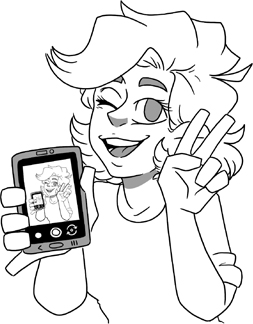

你的朋友Amelia想借用你的手机。你同意了，只要她答应把手机还给你。随后Benny来了，向Amelia借你的手机。Amelia把手机交给Benny，但让他答应把手机还给你。Benny还拿着手机时，Chantal又来借，然后是Dominykas、Edsger、Felistas，等等。如果这件事永远持续下去，你就永远拿不回手机。然而，看起来每个朋友都通过与另一个人约定由后者归还手机，履行了归还手机的承诺。如果允许无休止的重复，即使每次行为本身看似有理，我们也得不到期望的结果。Your friend Amelia wants to borrow your phone. You agree, so long as Amelia promises to get it back to you. Then, Benny comes along and asks Amelia to borrow your phone. Amelia gives Benny the phone, but makes Benny promise to give it back to you. While Benny still has the phone, Chantal asks to borrow it, and then Dominykas, then Edsger, then Felistas, etc. If this goes on forever, you'll never get your phone back. Yet, it seems that each of your friends lives up to the promise to give the phone back by making an agreement with someone else to take it back. If we allow endless repetition, even of some behavior that seems justifiable by itself, then we don't achieve the results we're hoping for.

本章解释如何防止无休止的重复。This chapter explains how to prevent endless repetitions.

## 3.0. 无休止的问题3.0. The Endless Problem

下面五个小程序说明了为何需要考虑终止性。Here are five little programs that demonstrate the need for considering termination.

首先是一个声称返回实参两倍值的方法：First up is a method that claims to return a value equal to twice its argument:

**method** BadDouble(x: **int**) **returns** (d: **int**)

**ensures** d == 2 * x

{

**var** y := BadDouble(x - 1);

d := y + 2;

}

确实，如果递归调用把y设为x - 1的两倍，那么y + 2就是x的两倍。但每次递归调用都会导致另一次递归调用，所以，正如那些借手机的朋友的行为，这个方法不会终止。这称为*无限递归*。我们希望避免无限递归，因为说这样的方法正确计算了2 * x，似乎并无意义。Sure, if the recursive call sets y to twice x - 1, then y + 2 will be twice x. But each recursive call will result in yet another recursive call, so, akin to the activities of your phone-borrowing friends, this method will not terminate. This is called *infinite recursion*. We want to avoid infinite recursion, because it does not seem meaningful to say such a method correctly computes 2 * x.

第二个例子是一个声称返回其实参值的方法。还有什么比这更简单呢？As a second example, here is a method that claims to return the value of its argument. What could be simpler?

**method** PartialId(x: **int**) **returns** (y: **int**)

**ensures** y == x

{

**if** x % 2 == 0 {

y := x;

} **else** {

y := PartialId(x);

}

}

如果给定的x为偶数，这个方法会正确返回x。但如果x为奇数，方法就会接着调用一个声称返回其实参的方法（也就是它自己）。这里可以观察到，*如果*PartialId终止，它就给出正确结果。这称为*部分正确性*，意思是每个*会终止的*调用都是正确的，但并不表示所有调用确实都会终止。If the given x is even, then this method correctly returns x. But if x is odd, then the method proceeds by calling a method (namely, itself) that claims to return its argument. What we observe here is that *if* PartialId terminates, then it gives the right result. This is called *partial correctness*, which means that every *terminating* call is correct, but it does not says that all calls do indeed terminate.

上面的BadDouble也符合部分正确性。事实上，由于BadDouble*从不*终止，即使把它的赋值d := y + 2改为d := y + 5，甚至改成d := 1000，它仍然满足部分正确性。BadDouble above also adheres to partial correctness. In fact, since BadDouble *never* terminates, it would satisfy partial correctness also if you changed its assignment d := y + 2 to d := y + 5, or, for that matter, to d := 1000.

如果程序部分正确，*并且*始终终止，就称其*完全正确*。本书始终证明完全正确性。我们以前见过这些概念。如果把不终止视为一种崩溃，那么第2.9.0节的谓词𝒲ℒ𝒫〚S, Q⟧就表示S相对于Q部分正确。此外，𝒲𝒫〚S, **true**⟧表示S不崩溃地终止。因此，两者的合取表明完全正确性，这正是第2.9.0节中见过的等式所刻画的：A program is said to be *totally correct* if it is partially correct *and* always terminates. Throughout this book, we will prove total correctness. We have seen these concepts before. If you view non-termination as a form of crashing, then the predicate 𝒲ℒ𝒫〚S, Q⟧ from Section 2.9.0 says that S is partially correct with respect to Q. Furthermore, 𝒲𝒫〚S, **true**⟧ says that S terminates without crashing. So, the conjunction of these two shows total correctness, which is captured in the equation we saw in Section 2.9.0:

𝒲𝒫〚S, Q⟧ = 𝒲ℒ𝒫〚S, Q⟧ && 𝒲𝒫〚S, **true**⟧

第三个例子是一个非确定性方法，给定某个数的平方的猜测值，它声称计算出该数真正的平方：As a third example, here is a nondeterministic method that claims to compute the actual square of a number, given a guess of the same:

**method** Squarish(x: **int**, guess: **int**) **returns** (y: **int**)

**ensures** x * x == y

{

**if**

**case** guess == x * x => // good guess!

y := guess;

**case true** =>

y := Squarish(x, guess - 1);

**case true** =>

y := Squarish(x, guess + 1);

}

这个实现部分正确，它漫无目的的搜索也可能找到答案。然而，它并不*保证*终止。对于正确的程序，我们希望通过给出终止性*证明*，来提供这一保证。The implementation is partially correct and it could happen that its aimless search finds the answer. However, there is no *guarantee* of termination. For correct programs, we want to provide that guarantee by giving a *proof* of termination.

第四个例子试图确立不可能成立的条件。若不是那几个爱管闲事的小孩，它还真能蒙混过关——呃，我是说，若不是必须证明终止性的话。The fourth example tries to establish something impossible. And it would have gotten away with it, too, if it weren't for these meddling kids—uh, I mean, if it weren't for having to prove termination.

**method** Impossible(x: **int**) **returns** (y: **int**)

**ensures** y % 2 == 0 && y == 10 * x - 3

{

y := Impossible(x);

}

最后一个例子，考虑这个可疑的函数定义：As a final example, consider this dubious function definition:

**function** Dubious(): **int** {

1 + Dubious()

}

这里不仅出现无限递归，还潜藏着数学上的不一致。如果允许这样的定义，就能很容易地证明**false**，如下程序片段中的断言所提示的推理所示：Here, we're seeing not just a case of infinite recursion, but also a lurking mathematical inconsistency. If we admit a definition like this, then you could easily prove **false**, as is shown by the reasoning suggested by the assertions in this program snippet:

**var** a := Dubious();

**assert** a == Dubious(); // this is what the previous

// assignment establishes

// by expanding Dubious() to its body, the following

// assertion says the same thing as the previous assertion

**assert** a == 1 + Dubious();

// combine the previous two assertions

**assert** a == 1 + a;

// subtract a from both sides

**assert** 0 == 1;

// arithmetic

**assert false**;

证明**false**应当是不可能的，否则就意味着数学上的*不一致*。由此例可知，不应允许像Dubious()这样在数学上不一致的函数。避免函数定义不一致最常见的方法，就是证明函数会终止。It should not be possible to prove **false**—that would be a sign of a mathematical *inconsistency*. We conclude from this example that we should not admit functions like Dubious() that are mathematically inconsistent. The most common way to avoid inconsistently defined functions is to prove that the functions terminate.

总之，我们希望避免无限递归及其他形式的无限重复，避免不能保证终止的情况，也避免数学上的不一致。我们希望超越部分正确性，通过证明无崩溃性和终止性，达到完全正确性。接下来看如何做到。In summary, we want to avoid infinite recursion and other forms of infinite repetition, avoid non-guaranteed termination, and avoid mathematical inconsistencies. We want to go beyond partial correctness, proving freedom from crashes and proving termination to achieve total correctness. Next, let's see how we do that.

## 3.1. 避免无限递归3.1. Avoiding Infinite Recursion

作为例子，考虑著名的斐波那契函数：As an example, consider the well-known Fibonacci function:

**function** Fib(n: **nat**): **nat** {

**if** n < 2 **then** n **else** Fib(n - 2) + Fib(n - 1)

}

这个例子使用了一个新类型**nat**。它表示自然数，即0、1、2、……，也就是整数中的非负子集。（另一种在自然数上定义Fib的方式，是把n定义为**int**类型，并添加前置条件**requires** 0 <= n。两者效果相同，但使用**nat**类型更简短。）In this example, I used a new type, **nat**. It denotes the natural numbers, that is, 0, 1, 2, . . . —the non-negative subset of the integers. (An alternative way to define Fib on the natural numbers would be to define n of type **int** and to add a precondition **requires** 0 <= n. These are in effect the same, but using the type **nat** is shorter.)

函数Fib有两个递归调用：Fib(n-2)和Fib(n-1)。如果Fib调用自身，如何确信递归最终会结束？想象对Fib求值所产生的活动记录构成一张图。例如，下面是从Fib(701)的活动记录开始的图的一小部分：Function Fib has two recursive calls, Fib(n-2) and Fib(n-1). If Fib calls itself, how do we convince ourselves that the recursion will eventually end? Imagine a graph of the activation records that result from evaluating Fib. For example, here is a small portion of that graph starting with an activation record for Fib(701):

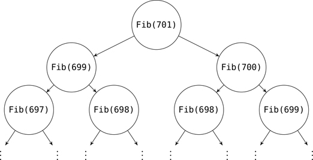

现在，想象给每个结点（即每个活动记录）标注某个自然数。为这些结点各选一个自然数的方便方法，是选择与Fib函数实参相同的数。如果图中每个结点的标注都严格小于其父结点的标注，那么图中的每条路径都有限。为什么？因为自然数不存在无限下降序列。（对此更常用的说法是无限下降*链*，从现在起我也将这样称呼。）Now, imagine decorating each node (that is, each activation record), with some natural number. A convenient way to pick such a natural number for each of these nodes is to pick the same number as the argument to the Fib function. If every node in the graph has the property that its decoration is strictly smaller than the decoration of the parent node, then every path in the graph is finite. Why? Because there is no infinite descending sequence of natural numbers. (The common phrase for this, which I'll use from now one, is infinite descending *chain*.)

这为验证函数终止提供了一种方法。为此，只需要一种机制为每个活动记录指定标注，再验证被调用者的标注严格小于调用者的标注。这种标注称为*终止性度量*。This gives us a way to verify that a function terminates. To pull this off, all we need is a mechanism to prescribe a decoration for each activation record, and then we need to verify that the decoration of the callee is strictly smaller than the decoration of the caller. A decoration like this is called a *termination metric*.

在Dafny中，为函数或方法指定终止性度量的方式，是使用**decreases**子句。对于Fib，写成：In Dafny, the way to prescribe a termination metric for a function or method is to use a **decreases** clause. For Fib, we write:

**function** Fib(n: **nat**): **nat**

**decreases** n

{

**if** n < 2 **then** n **else** Fib(n - 2) + Fib(n - 1)

}

**decreases**关键字之后的表达式（这里是表达式n）会被求值，并用作Fib(n)活动记录的标注。因此，两个递归调用所产生的活动记录的标注，分别为n-2和n-1。Dafny为第一个调用生成并检查证明义务n-2 < n，为第二个调用生成并检查n-1 < n。这些证明义务意味着Fib的递归会终止。The expression that follows the **decreases** keyword (here, the expression n) will be evaluated and used as the decoration for the activation record of Fib(n). The decorations for the activation records that result from the two recursive calls are therefore n-2 and n-1, respectively. Dafny generates and checks the proof obligation n-2 < n for the first call and n-1 < n for the second call. These proof obligations imply that Fib's recursion terminates.

许多时候，**decreases**子句可以直观地解读为：“每次递归调用Fib时，实参n都会减小。”不过要注意，关键字**decreases**只是在说明如何标注活动记录。根据进入函数或方法时求值的**decreases**子句，活动记录一旦获得标注，该标注便不再改变。必须体现减小的是调用者标注与被调用者标注之间的*关系*。In many cases, the **decreases** clause gives rise to an intuitive reading: “with each recursive call of Fib, the argument n decreases”. However, note that the keyword **decreases** just says how to decorate an activation record. Once the activation record gets decorated, according to the **decreases** clause evaluated on entry to the function or method, the decoration does not change. It is the *relation* between the caller's decoration and the callee's decoration that must show a decrease.

还有许多其他方式可以标注Fib的活动记录，以证明终止性。例如，也可以使用There are many other ways to decorate the activation records of Fib to prove termination. For example, we could have used

**decreases** 3*n + 2

再考虑一个例子。下面的函数计算整数序列中索引lo到hi之间的元素之和：Let's consider another example. Here is a function that computes the sum of the elements of an integer sequence from index lo to hi:

**function** SeqSum(s: **seq**<**int**>, lo: **int**, hi: **int**): **int**

**requires** 0 <= lo <= hi <= |s|

**decreases** hi - lo

{

**if** lo == hi **then** 0 **else** s[lo] + SeqSum(s, lo + 1, hi)

}

这个例子初步展示了Dafny的**seq**类型，它表示不可变的元素序列。序列s的长度由|s|给出；对于满足0 <= i < |s|的索引i，可用表达式s[i]取得该位置的元素。后续各章会更多地使用序列。This example gives a taste of Dafny's **seq** type, which denotes immutable sequences of elements. The length of a sequence s is given by |s| and the element at index i, where 0 <= i < |s|, is retrieved by the expression s[i]. Later chapters will make more use of sequences.

SeqSum函数需要用稍复杂的方式计算终止性度量。所给的**decreases**子句确实给出了一个每次递归调用都会减小的表达式。具体而言，递归调用具有证明义务hi - (lo+1) < hi - lo。The SeqSum function needs a slightly more complicated way of computing its termination metric. The given **decreases** clause does indeed give an expression that decreases with each recursive call. In particular, the recursive call has the proof obligation hi - (lo+1) < hi - lo.

既然-(lo+1) < -lo，能否只选择-lo作为计算终止性度量的方式？这种度量的问题在于，如果不限制在整数的非负子集内，就*确实存在*无限下降链，因此无法得出递归终止的结论。对于SeqSum中这样的递归调用，Dafny会检查调用者的终止性度量非负。因此，如果尝试**decreases** -lo，就会得到Dafny无法验证终止性的错误消息。How about instead choosing just -lo as the way to compute termination metrics, since, after all, -(lo+1) < -lo? The problem with such a termination measure is that if we don't stay within the non-negative subset of the integers, then there *are* infinite decreasing chains, so we cannot conclude that the recursion terminates. At a recursive call like the one in SeqSum, Dafny checks that the termination metric of the caller is non-negative. If you try **decreases** -lo, you will therefore get an error message that Dafny cannot verify termination.

## 习题3.0。Exercise 3.0.

编写一个**decreases**子句，证明以下函数的终止性：Write a **decreases** clause that proves the termination of the following function:

**function** F(x: **int**): **int** {

**if** x < 10 **then** x **else** F(x - 1)

}

## 习题3.1。Exercise 3.1.

编写一个**decreases**子句，证明以下函数的终止性：Write a **decreases** clause that proves the termination of the following function:

**function** G(x: **int**): **int** {

**if** 0 <= x **then** G(x - 2) **else** x

}

## 习题3.2。Exercise 3.2.

编写一个**decreases**子句，证明以下函数的终止性：Write a **decreases** clause that proves the termination of the following function:

**function** H(x: **int**): **int** {

**if** x < -60 **then** x **else** H(x - 1)

}

## 习题3.3。Exercise 3.3.

编写一个**decreases**子句，证明以下函数的终止性：Write a **decreases** clause that proves the termination of the following function:

**function** I(x: **nat**, y: **nat**): **int** {

**if** x == 0 || y == 0 **then**

12

**else if** x % 2 == y % 2 **then**

I(x - 1, y)

**else**

I(x, y - 1)

}

## 边栏3.0Sidebar 3.0

如果需要走5步，旅程中就有6个位置：任何时刻，你可能已经走了0、1、2、3、4步，或全部5步。下面各图分别显示走了0步、2步和5步后的进度：If you have 5 steps to make, there are 6 places along your journey: at any time, you may have taken 0, 1, 2, 3, 4, or all 5 steps. These diagrams depict your progress after 0 steps, 2 steps, and 5 steps, respectively:

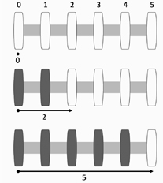

如果n表示已经走过的步数，则有If n denotes the steps you've taken, we have

0 <= n <= 5

也就是说，n最小可为0，最大可为5。注意，上下界都包含在内（即使用<=而非<）。当你表示已完成多少，也就是目前的进度时，得到的就是这种区间。That is, n can be as small as 0 and as large as 5. Notice the inclusive upper and lower bounds (that is, <= as opposed to <). That's the kind of interval you get when you express how much has been done, that is, your progress so far.

更一般地，如果旅程共有N步，就有N + 1种不同的进度。More generally, if there are N steps along your journey, there are N + 1 different measures of progress.

从lo开始、到hi结束的旅程（如函数SeqSum要累加的序列元素区间），共有hi - lo步。沿途有hi + 1 - lo种不同进度。例如，对SeqSum(s, 0, 5)求值时，我们对5 - 0个元素求和，总共会对SeqSum的函数体求值6次。A journey that starts at lo and ends at hi (as in the interval of sequence elements to be added by function SeqSum) has hi - lo steps. There are hi + 1 - lo different measures of progress along the way. For example, during the evaluation of SeqSum(s, 0, 5), we're summing 5 - 0 elements and we will evaluate the body of SeqSum a total of 6 times.

## 习题3.4。Exercise 3.4.

编写一个**decreases**子句，证明以下函数的终止性：Write a **decreases** clause that proves the termination of the following function:

**function** J(x: **nat**, y: **nat**): **int** {

**if** x == 0 **then**

y

**else if** y == 0 **then**

J(x - 1, 3)

**else**

J(x, y - 1)

}

## 习题3.5。Exercise 3.5.

编写一个**decreases**子句，证明以下函数的终止性：Write a **decreases** clause that proves the termination of the following function:

**function** K(x: **nat**, y: **nat**, z: **nat**): **int** {

**if** x < 10 || y < 5 **then**

x + y

**else if** z == 0 **then**

K(x - 1, y, 5)

**else**

K(x, y - 1, z - 1)

}

## 习题3.6。Exercise 3.6.

编写一个**decreases**子句，证明以下函数的终止性：Write a **decreases** clause that proves the termination of the following function:

**function** L(x: **int**): **int** {

**if** x < 100 **then** L(x + 1) + 10 **else** x

}

## 习题3.7。Exercise 3.7.

以下函数计算*霍夫施塔特G序列*：The following function computes the *Hofstadter G sequence*:

**function** G(n: **nat**): **nat** {

**if** n == 0 **then** 0 **else** n - G(G(n - 1))

}

找出适当的**decreases**子句，证明G终止。Find an appropriate **decreases** clause to prove that G terminates.

## 3.2. 良基关系3.2. Well-Founded Relations

终止性度量并不限于自然数。只要所用的“小于”关系是*良基的*（稍后定义），上述技术就能用于证明终止性。我用记号≻表示良基序，其中较小元素写在右边。也就是说，对这个序，我改用“大于”记法，而不是“小于”记法。这样就能从调用者的终止性度量（左边）想到被调用者的终止性度量（右边）。可以把*a* ≻ *b*读作“*a*大于*b*”“*a*下降到*b*”或“*a*约减到*b*”。Termination metrics are not restricted to natural numbers. As long as the “less than” relation we use is *well-founded* (which I will define in a moment), the technique I discussed above lets you prove termination. I will use the notation ≻ for a well-founded order, where the smaller element goes on the right. That is, for this ordering, I'm switching to a “greater than” notation instead of a “less than” notation. This lets us think of going from the caller's termination metric (on the left) to the callee's termination metric (on the right). You can pronounce *a* ≻ *b* as “*a* exceeds *b*”, “*a* goes down to *b*”, or “*a* reduces to *b*”.

二元关系≻在以下三个条件成立时称为*良基的*：A binary relation ≻ is *well-founded* when the following three conditions hold:

- ≻具有*反自反性*：该关系从不使元素与自身相关联。用公式表示，*a* ≻ *a* ≻ is *irreflexive*: The relation never relates an element to itself. In formulas, *a* ≻ *a*

  对任何*a*都不成立。never holds for any *a*.
- ≻具有*传递性*：对于任意*a*、*b*和*c*，只要*a* ≻ *b*和*b* ≻ *c*成立，*a* ≻ *c*就也成立。≻ is *transitive*: Whenever *a* ≻ *b* and *b* ≻ *c* hold, then so does *a* ≻ *c*, for any *a*, *b*, and *c*.
- ≻满足*下降链条件*：该关系没有*无限下降链*，也就是说，不存在无限值序列*a*<sub>0</sub>*, a*<sub>1</sub>*, a*<sub>2</sub>*, . . .*使得≻ satisfies the *descending chain condition*: The relation has no *infinite descending chain*, that is, there is no infinite sequence of values *a*<sub>0</sub>*, a*<sub>1</sub>*, a*<sub>2</sub>*, . . .* such that

a<sub>0</sub> ≻ a<sub>1</sub> ≻ a<sub>2</sub> ≻ · · ·

满足前两个条件的关系称为*严格偏序*（有时也称*反自反偏序*）。*偏*序允许并非所有元素之间都有序关系。例如，可能存在元素*a*和*b*，使*a* ≻ *b*与*b* ≻ *a*都不成立。（如果对于每一对不同的值a和b，都有*a* ≻ *b*或*b* ≻ *a*成立，那么该严格序称为*全序*。）因此，良基关系就是还满足下降链条件的严格偏序。<sup>2</sup>A relation that satisfies the first two conditions is called a *strict partial order* (or, sometimes, an *irreflexive partial order*). Being a *partial* order allows the possibility of not ordering all elements. For example, there may be elements *a* and *b* such that neither *a* ≻ *b* nor *b* ≻ *a* holds. (If either *a* ≻ *b* or *b* ≻ *a* does hold for every pair of distinct values a and b, then the strict order is called *total*.) So, a well-founded relation is a strict partial order that additionally satisfies the descending chain condition.<sup>2</sup>

将自然数上的序推广为程序中所有类型的值上的良基序≻，便得到证明不存在无限递归的以下方法：给每个活动记录标注一个值（可为任意类型），使每次调用中，调用者的标注*a*与被调用者的标注*b*满足*a* ≻ *b*。Generalizing from the ordering on natural numbers to a well-founded order ≻ on the values of all types in our program, we have the following recipe for proving that there is no infinite recursion: Decorate every activation record with a value (of any type) so that, for every call, the caller's decoration *a* and callee's decorations *b* satisfy *a* ≻ *b*.

本书始终使用同一个固定的良基关系≻，即Dafny使用的关系。Dafny为每种类型预定义了≻，有时还为不同类型的值之间定义它（不过在大多数情况下，不同类型的值在这个偏序中没有关系）。We are going to use one, fixed well-founded relation ≻ throughout this book, namely the one that Dafny uses. Dafny pre-defines ≻ for each type, and in some cases also for values between different types (but in most cases, values from different types are not related in this partial order).

下面是Dafny某些类型内置的良基关系：Here are the built-in well-founded relations for some of Dafny's types:

| X**和**y**的类型****type of** X **and** y |  | **X** ≻ **y**（“X约减到y”）**X** ≻ **y** (“X reduces to y”) |
| --- | --- | --- |
| **bool** |  | X && !y |
| **int** |  | y < X && 0 <= X |
| **real** |  | y <= X - 1.0 && 0.0 <= X |
| **set**<T> |  | y是X的真子集y is a proper subset of X |
| **seq**<T> |  | y是X的连续真子序列y is a consecutive proper sub-sequence of X |
| 归纳数据类型inductive datatypes |  | y在结构上包含于Xy is structurally included in X |

有几点需要说明。对于布尔值，序关系规定，减小的唯一方式是从**true**到**false**。Dafny在整数上的良基关系把非负数排在负数之上，但负数彼此之间不排序。如果把整数的y < X看作y <= X - 1，那么整数和实数上的关系实际上相同。注意，y < X && 0.0 <= X不是实数上的良基序，因为该序存在无限下降链。第4章将讨论归纳数据类型（第4.3节讨论结构包含）。Some remarks are in order. For booleans, the ordering says that the only way to decrease is from **true** to **false**. Dafny's well-founded relation on integers orders nonnegative numbers above negative numbers, but the negative numbers themselves are not ordered. The relations on integers and reals are really the same, if you think of y < X for integers as y <= X - 1. Note that y < X && 0.0 <= X would not be a well-founded order on the reals, because this order has infinite descending chains. We'll talk about inductive datatypes in Chapter 4 (and Section 4.3 talks about structural inclusion).

## 习题3.8。Exercise 3.8.

编写一个**decreases**子句，证明以下函数的终止性：Write a **decreases** clause that proves the termination of the following function:

**function** M(x: **int**, b: **bool**): **int** {

**if** b **then** x **else** M(x + 25, **true**)

}

## 习题3.9。Exercise 3.9.

编写一个**decreases**子句，证明以下函数的终止性：Write a **decreases** clause that proves the termination of the following function:

**function** N(x: **int**, y: **int**, b: **bool**): **int** {

**if** x <= 0 || y <= 0 **then**

x + y

**else if** b **then**

N(x, y + 3, !b)

**else**

N(x - 1, y, **true**)

}

## 习题3.10。Exercise 3.10.

习题3.1的一个答案是**decreases** x。(a) 用≻写出终止性证明义务。(b) 针对**int**类型展开这个≻。An answer to Exercise 3.1 is **decreases** x. (a) Write the termination proof obligation using ≻. (b) Expand this ≻ for type **int**.

## 3.3. 字典序元组3.3. Lexicographic Tuples

证明终止性时，有时有必要或适宜使用*字典序元组*。元组是一列值，例如二元组或三元组。元组上的*字典序*逐分量比较，位置靠前的分量被视为更重要。例如，对于自然数的二元组，4,12大于4,11、4,2、3,525600和2,0。4,12大于4,2，是因为第一个分量相等，而第二个分量从12下降到2。4,12大于3,525600，是因为第一个分量从4下降到3，因此第二个分量无关紧要。Sometimes when proving termination, it is necessary or convenient to use a *lexicographic tuple*. A tuple is a list of values, like a pair or a triple. The *lexicographic order* on tuples is a component-wise comparison where earlier components are treated as more significant. For example, for pairs of natural numbers, we have that 4,12 exceeds 4,11 and 4,2 and 3,525600 and 2,0. The reason that 4,12 exceeds 4,2 is that the first components are equal and, for the second component, 12 goes down to 2. The reason that 4,12 exceeds 3,525600 is that 4 goes down to 3 in the first component, so the second component does not matter.

甚至可以比较长度不同的元组。例如，二元组可以与四元组比较，16元组可以与三元组比较。这时，如果一个是另一个的真前缀，那么*较短*的元组大于另一个；否则，只比较双方共有位置的分量，就能得到答案。例如，4,6,0大于4,6,0,25,3，因为4,6,0是4,6,0,25,3的真前缀；而2,5大于1，因为前缀2大于前缀1。We can even compare tuples of different lengths. For example, we can compare a pair with a quadruple or compare a 16-tuple with a triple. In these cases, if one is a proper prefix of the other, then the *shorter* tuple exceeds the other; otherwise, comparing as many components as they have in common gives you the answer. For example, 4,6,0 exceeds 4,6,0,25,3, because 4,6,0 is a proper prefix of 4,6,0,25,3, and 2,5 exceeds 1, because the prefix 2 exceeds the prefix 1.

如果给元组长度规定某个上界，那么上述字典序的良基性就可以由各分量序的良基性推出。If we impose some upper bound on the length of tuples, then the well-foundedness of the lexicographic order defined above follows from the well-foundedness of the component-wise orders.

为了在终止性证明中使用字典序元组，Dafny允许每个**decreases**子句给出一*列*表达式。虽然**decreases**子句可列出的表达式数量没有限制，但任何给定程序都有某个长度最大的**decreases**子句。因此，所用的字典序确实是良基的。我既用≻表示元组的字典序，也用它表示各分量上的序。To allow lexicographic tuples in proofs of termination, Dafny allows each **decreases** clause to give a *list* of expressions. Although there is no limit on how many expressions a **decreases** clause can list, any given program has some maximum-length **decreases** clause. Therefore, the lexicographic order we use is indeed well-founded. I will write ≻ for the lexicographic order on tuples as well as for the order on each component.

## 习题3.11。Exercise 3.11.

判断第一个元组是否大于第二个元组。Determine if the first tuple exceeds the second.

| a) | 2,5与1,72,5 and 1,7 |
| --- | --- |
| b) | 1,7与7,11,7 and 7,1 |
| c) | 5,0,8与4,935,0,8 and 4,93 |
| d) | 4,9,3与4,934,9,3 and 4,93 |
| e) | 4,93与4,9,34,93 and 4,9,3 |
| f) | 3与2,93 and 2,9 |
| g) | **true**,80与**false**,66**true**,80 and **false**,66 |
| h) | **true**,2与19,1**true**,2 and 19,1 |
| i) | 4,**true**,50与4,**false**,8004,**true**,50 and 4,**false**,800 |
| j) | 7.0,{3,4,9},**false**,10与7.0,{3,9},**true**,107.0,{3,4,9},**false**,10 and 7.0,{3,9},**true**,10 |

在(j)中，表达式{3,4,9}和{3,9}表示集合。In (j), the expressions {3,4,9} and {3,9} denote sets.

接下来，再展示一些使用字典序元组的例子。Next, I will show some more examples that use lexicographic tuples.

### 3.3.0. 剩余学业3.3.0. Remaining school work

假设你还剩n门课程才能毕业。开始新课程c时，调用方法Suppose you have n courses left before graduation. When you start a new course c, a call to the method

**method** RequiredStudyTime(c: **nat**) **returns** (hours: **nat**)

会告诉你完成该课程需要学习多少小时。课程具体涵盖什么内容取决于教师，因此对于输出参数hours，无法作出更精确的说明。tells you how many hours of studying is needed to complete the course. Exactly which material will be covered in the course depends on the teacher, so there is nothing more precise we can say about the out-parameter hours.

下面的方法模拟毕业之前的学习过程。它表示，你在课程n中还剩h小时，之后还要完成从0到n的课程。The following method simulates your time until graduation. It says you have h hours left in course n, after which you also have to complete courses 0 to n.

**method** Study(n: **nat**, h: **nat**)

**decreases** n, h

{

**if** h != 0 {

// first, study for an hour, and then:

Study(n, h - 1);

} **else if** n == 0 {

// you just finished course 0 - woot woot, graduation time!

} **else** {

// find out how much studying is needed for the next course

**var** hours := RequiredStudyTime(n - 1);

// get started with course n-1:

Study(n - 1, hours);

}

}

证明Study终止，需要字典序元组。来看看**decreases** n, h如何证明终止性。这里有两个递归调用。对于第一个，需要证明To prove termination of Study, we need a lexicographic tuple. Let's see how the **decreases** n, h proves termination. There are two recursive calls. For the first one, we need to prove

n, h ≻ n, h-1

对于另一个，需要证明and for the other, we need to prove

n, h ≻ n-1, hours

这两个条件都成立，因此可知方法Study终止。Both of these conditions hold, so it follows that method Study terminates.

## 习题3.12。Exercise 3.12.

假设大学严加要求教授，将每门课程所需学习时间限制为200。这时就能为方法RequiredStudy-Time写出后置条件：Suppose the university cracks down on professors to limit the required study time for a course to 200. We can then write a postcondition for method RequiredStudy-Time:

**method** RequiredStudyTime(c: **nat**) **returns** (hours: **nat**)

**ensures** hours <= 200

知道这个界限后，仍然可以为Study使用终止性度量n,h，但也可以写出不使用字典序元组的终止性度量。请写出这样的度量。Knowing such a bound, you can still use the termination metric n,h for Study, but it's also possible to write a termination metric without using a lexicographic tuple. Do so.

### 3.3.1. Ackermann函数3.3.1. Ackermann

下一个例子是著名的Ackermann函数。它会运行很长时间，但确实终止。如果使用字典序二元组，就很容易证明终止性。The next example is the famous Ackermann function. It runs for a long time, but it does terminate. Proving termination is easy if we use a lexicographic pair.

**function** Ack(m: **nat**, n: **nat**): **nat**

**decreases** m, n

{

**if** m == 0 **then**

n + 1

**else if** n == 0 **then**

Ack(m - 1, 1)

**else**

Ack(m - 1, Ack(m, n - 1))

}

检查终止性时，要检查每次递归调用中，自然数字典序二元组m, n都减小。第二个分支中的递归调用，以及第三个分支中的外层递归调用，都以m - 1为第一个实参，因此减小了二元组m, n的第一个分量。对于第三个分支中的内层递归调用，m, n大于m, n - 1。因此，终止性得证。To check termination, we check that the lexicographic pair m, n of natural numbers decreases for each recursive call. The recursive call in the second branch and the outer recursive call in the third branch use m - 1 as the first argument, thus decreasing the first component of the pair m, n. For the inner recursive call in the third branch, we have that m, n exceeds m, n - 1. Thus, we have proved termination.

## 边栏3.1Sidebar 3.1

在Dafny的终止性证明中使用字典序元组时，要在**decreases**关键字之后列出元组分量。Dafny也支持元组类型，但它们是内置的归纳数据类型，因此按照结构包含排序。所以，**decreases** E, F表示用字典序二元组E,F作为终止性度量，而**decreases** (E,F)则表示使用单个值(E,F)。To use a lexicographic tuple in a termination proof in Dafny, list the components of the tuple after the **decreases** keyword. Dafny also supports tuple types, but they are built-in inductive datatypes, so they are ordered by structural inclusion. So, whereas **decreases** E, F says to use the lexicographic pair E,F as the termination metric, **decreases** (E,F) says to use the single value (E,F).

按照字典序，有**true**,5 ≻ **false**，因为第一个分量**true**下降为**false**。还有({2,4,6},**true**) ≻ {2,4,6}，因为集合{2,4,6}在结构上包含于二元组({2,4,6},**true**)。然而，(**true**,5) ≻ **false**和{2,4,6},**true** ≻ {2,4,6}都不成立。We have that **true**,5 ≻ **false** in lexicographic order, because the first component **true** goes down to **false**. We also have ({2,4,6},**true**) ≻ {2,4,6}, because the set {2,4,6} is structurally included in the pair ({2,4,6},**true**). However, neither (**true**,5) ≻ **false** nor {2,4,6},**true** ≻ {2,4,6} holds.

### 3.3.2. 相互递归的方法3.3.2. Mutually recursive methods

相互递归的方法中有一种常见模式：可将其中一个方法视为调用“内层”计算的“外层”计算。第3.3.0节中Study例子的一个变体展示了这种模式。这里，用n表示40门课程中*已经完成*的课程数，用h表示当前课程剩余的小时数。One common pattern among mutually recursive methods is that one of the methods can be considered as an “outer” computation that calls an “inner” computation. A variation of the Study example from Section 3.3.0 shows this pattern. Here, I'm using n as the number of courses *completed*, out of 40, and h as the number of hours remaining for the current class.

**method** StudyPlan(n: **nat**)

**requires** n <= 40

**decreases** 40 - n

{

**if** n == 40 {

// done

} **else** {

**var** hours := RequiredStudyTime(n);

Learn(n, hours);

}

}

**method** Learn(n: **nat**, h: **nat**)

**requires** n < 40

**decreases** 40 - n, h

{

**if** h == 0 {

// done with class n; continue with the rest of the study plan

StudyPlan(n + 1);

} **else** {

// some learning to take place here…

Learn(n, h - 1);

}

}

方法StudyPlan是“外层”方法，Learn是“内层”方法。Method StudyPlan is the “outer” method and Learn is the “inner” method.

使用给定的**decreases**子句，终止性证明义务如下：With the given **decreases** clauses, the proof obligations for termination are as follows:

| **调用****call** | **确立终止性的证明义务****proof obligation for establishing termination** |
| --- | --- |
| StudyPlan调用LearnStudyPlan calls Learn | 40 - n ≻ 40 - n, h |
| Learn调用StudyPlanLearn calls StudyPlan | 40 - n, h ≻ 40 - (n + 1) |
| Learn调用LearnLearn calls Learn | 40 - n, h ≻ 40 - n, h - 1 |

对于第一个调用，证明义务成立，是因为40-n是40-n, hours的真前缀。对于第二个调用，证明义务成立，是因为第一个分量减小。对于第三个调用，第一个分量保持不变，第二个分量减小。因此，两个方法都会终止。For the first call, the proof obligation holds because 40-n is a proper prefix of 40-n, hours. For the second call, the proof obligation holds because the first component is decreased. For the third call, the first component stays the same and the second component decreases. So, the two methods terminate.

## 习题3.13。Exercise 3.13.

为上述外层/内层StudyPlan程序的以下变体添加**decreases**子句，证明其终止性。Add **decreases** clauses to prove termination of the following variation of the outer/inner StudyPlan program from above.

**method** Outer(a: **nat**) {

**if** a != 0 {

**var** b := RequiredStudyTime(a - 1);

Inner(a, b);

}

}

**method** Inner(a: **nat**, b: **nat**)

**requires** 1 <= a

{

**if** b == 0 {

Outer(a - 1);

} **else** {

Inner(a, b - 1);

}

}

## 习题3.14。Exercise 3.14.

为上述外层/内层StudyPlan程序的以下变体添加**decreases**子句，证明其终止性。Add **decreases** clauses to prove termination of the following variation of the outer-inner StudyPlan program from above.

**method** Outer(a: **nat**) {

**if** a != 0 {

**var** b := RequiredStudyTime(a - 1);

Inner(a - 1, b);

}

}

**method** Inner(a: **nat**, b: **nat**) {

**if** b == 0 {

Outer(a);

} **else** {

Inner(a, b - 1);

}

}

### 3.3.3. 重构子计算3.3.3. Refactor a subcomputation

下面的例子说明字典序元组的一种实用技巧。考虑以下计算2<sup>n</sup> - 1的函数：Here's an example that illustrates a useful trick with lexicographic tuples. Consider the following function, which computes 2<sup>n</sup> - 1:

**function** ExpLess1(n: **nat**): **nat** {

**if** n == 0 **then** 0 **else** 2 * ExpLess1(n - 1) + 1

}

很容易看出ExpLess1终止，因为它减小了n。现在，假设要将**else**分支的计算重构为计算2<sup>n</sup> - 2的函数ExpLess2(n)：It is easy to see that ExpLess1 terminates, because it decreases n. Now, suppose that we want to refactor the computation of the **else** branch into a function ExpLess2(n) that computes 2<sup>n</sup> - 2:

**function** ExpLess1(n: **nat**): **nat** {

**if** n == 0 **then** 0 **else** ExpLess2(n) + 1 // what about

// termination of the call to ExpLess2?

}

**function** ExpLess2(n: **nat**): **nat**

**requires** 1 <= n

{

2 * ExpLess1(n - 1)

}

显然，这种重构不改变ExpLess1所做的事，因此我们预期ExpLess1仍然终止。但如何*证明*相互递归的ExpLess1和ExpLess2终止？Clearly, this refactoring does not alter what ExpLess1 does, so we expect that ExpLess1 still terminates. But how do we *prove* termination of the mutually recursive ExpLess1 and ExpLess2?

如果两个函数都声明**decreases** n，就能证明从ExpLess2到ExpLess1的调用终止，但无法证明从ExpLess1到ExpLess2的调用终止，因为它传入相同的n值。如果改为对ExpLess1使用**decreases** n，对ExpLess2使用**decreases** n-1，就能证明从ExpLess1到ExpLess2的调用终止，却无法证明从ExpLess2到ExpLess1的调用终止。If we declare both functions with **decreases** n, we can prove termination of the call from ExpLess2 to ExpLess1, but not of the call from ExpLess1 to ExpLess2, since it passes the same value for n. If we instead try **decreases** n for ExpLess1 and **decreases** n-1 for ExpLess2, then we can prove termination of the call from ExpLess1 to ExpLess2, but not of the call from ExpLess2 to ExpLess1.

在这种一个函数以相同参数值调用另一个函数的情况下，我们希望把其中一个函数排在另一个“下面”。可以通过给字典序元组添加第二个分量来做到。第二个分量的值具体是什么无关紧要，只要ExpLess1的值大于ExpLess2的值即可。最直接的做法如下：In a situation like this, when one function calls another with the same parameter values, we would like to order one of the functions “below” the other. We can do that by adding a second component to the lexicographic tuple. It doesn't matter what the values of the second component is, as long as the value is greater for ExpLess1 than it is for ExpLess2. Here is the most straightforward way to do it:

**function** ExpLess1(n: **nat**): **nat**

**decreases** n, 1

{

**if** n == 0 **then** 0 **else** ExpLess2(n) + 1

}

**function** ExpLess2(n: **nat**): **nat**

**requires** 1 <= n

**decreases** n, 0

{

2 * ExpLess1(n - 1)

}

把这个规约读出来时，“减小1”可能显得违反直觉，因为1是常量。但请记住，**decreases**子句只是规定如何计算函数活动记录标注的一种方式。也就是说，**decreases**子句实际上只是在说：“我想这样计算这个函数的终止性度量。”按照终止性检查规则，很容易看出这些**decreases**子句确实证明了终止性：When you read this specification out loud, it may feel counterintuitive to “decrease 1”, since 1 is a constant. But remember, the **decreases** clause is just a way to prescribe how to compute the decorations of the function's activation records. That is, the **decreases** clause really just says “here's how I want to compute the termination metric for this function”. Following our rules for checking termination, it is easy to see that these **decreases** clauses do indeed prove termination:

| **调用****call** | **确立终止性的证明义务****proof obligation for establishing termination** |
| --- | --- |
| ExpLess1调用ExpLess2ExpLess1 calls ExpLess2 | n, 1 ≻ n, 0 |
| ExpLess2调用ExpLess1ExpLess2 calls ExpLess1 | n, 0 ≻ n - 1, 1 |

事实上，由于元组的真前缀大于元组本身，也可以为ExpLess1选择**decreases** n，为ExpLess2选择**decreases** n, 257。In fact, because of the rule that a proper prefix of a tuple exceeds the tuple itself, we could also have chosen **decreases** n for ExpLess1 and **decreases** n, 257 for ExpLess2.

## 习题3.15。Exercise 3.15.

以下函数F和M计算*霍夫施塔特雌雄序列*。The following functions F and M compute *Hofstadter Female and Male sequences*.

**function** F(n: **nat**): **nat** {

**if** n == 0 **then** 1 **else** n - M(F(n - 1))

}

**function** M(n: **nat**): **nat** {

**if** n == 0 **then** 0 **else** n - F(M(n - 1))

}

找出**decreases**子句，证明F和M终止。Find **decreases** clauses that prove termination of F and M.

## 习题3.16。Exercise 3.16.

上面第3.3.2节中的StudyPlan例子，利用了真前缀大于较长字典序元组的规则。为StudyPlan和Learn编写**decreases**子句，不使用该规则而证明终止性。也就是说，StudyPlan和Learn的**decreases**子句将具有相同长度。The StudyPlan example in Section 3.3.2 above benefited from the rule that a proper prefix exceeds a longer lexicographic tuple. Write **decreases** clauses for StudyPlan and Learn that prove termination without making use of that rule. That is, your **decreases** clauses for StudyPlan and Learn will be equally long.

## 习题3.17。Exercise 3.17.

找出一个**decreases**子句，证明以下函数的终止性。（这题有些难。）Find a **decreases** clause that proves the termination of the following function. (This one is tricky.)

**function** F(x: **nat**, y: **nat**): **int** {

**if** 1000 <= x **then**

x + y

**else if** x % 2 == 0 **then**

F(x + 2, y + 1)

**else if** x < 6 **then**

F(2 * y, y)

**else**

F(x - 4, y + 3)

}

## 3.4. Dafny中默认的decreases3.4. Default decreases in Dafny

在Dafny中，如果递归函数或方法没有显式给出**decreases**子句，验证器就会自行给出一个。大体而言，这个默认终止性度量是按给定顺序排列的函数或方法参数构成的字典序元组。In Dafny, if a recursive function or method is not given an explicit **decreases** clause, the verifier makes one up. More or less, this default termination metric is the lexicographic tuple of the function or method's parameters, in the order given.

例如，下面给出本章若干例子的签名，显示在未手工提供**decreases**子句时，它们会获得怎样的默认**decreases**。For example, here are the signatures of some of the examples in this chapter, showing which default **decreases** they would get if no **decreases** clause is supplied manually.

**function** Fib(n: **nat**): **nat**

**decreases** n

**function** SeqSum(s: **seq**<**int**>, lo: **int**, hi: **int**): **int**

**decreases** s, lo, hi

**method** Study(n: **nat**, h: **nat**)

**decreases** n, h

**function** Ack(m: **nat**, n: **nat**): **nat**

**decreases** m, n

**method** StudyPlan(n: **nat**)

**decreases** n

**method** Outer(a: **nat**) // from Exercise 3.13

**decreases** a

**method** Inner(a: **nat**, b: **nat**) // from Exercise 3.13

**decreases** a, b

SeqSum的默认终止性度量不适合证明终止性（它需要hi - lo），因此必须手工提供**decreases**子句。StudyPlan也是如此，它需要终止性度量40 - n。但对其他例子，默认**decreases**子句是正确的，因此即使省略**decreases**子句，验证器也会自动证明终止性，而不要求再提供任何内容。The default termination metric for SeqSum is not right for proving termination (it needs hi - lo), so a **decreases** clause has to be supplied manually. The same goes for StudyPlan, which needs the termination metric 40 - n. But for the others, the default **decreases** clause is correct, so if you omitted the **decreases** clause, the verifier would prove termination automatically without prompting you to supply anything else.

我告诉你的是默认**decreases**子句*大致*是什么。精确规则稍微复杂一些。幸运的是，这些细节不重要，因为Dafny IDE会在悬停文本中告诉你所选内容。因此，无须记住Dafny得出默认**decreases**子句的精确规则，只需查看实际使用的内容即可。I told you *more or less* what the default **decreases** clause is. The exact rules are slightly more involved. Luckily, those details are not important, because the Dafny IDEs tell you in hover text what gets chosen. So, rather than memorizing the exact rule that Dafny uses to arrive at a default **decreases** clause, you can simply inspect what gets used.

还应记住，默认**decreases**子句只是一次简单猜测。不过，这个猜测在实践中往往有效。在本书其余部分，只要Dafny猜对，我就会省略**decreases**子句。It is also good to remember that the default **decreases** clause is merely a simple guess. Nevertheless, this guess very often works in practice. In the rest of this book, I will omit **decreases** clauses when Dafny guesses correctly.

## 习题3.18。Exercise 3.18.

尝试删除本章各例子中显式的**decreases**子句。Dafny能为哪些例子猜对？查看悬停文本，检查Dafny猜测了什么。Try removing the explicit **decreases** clauses in the examples shown in this chapter. Which of them does Dafny guess correctly? Check the hover text to inspect what Dafny guesses.

## 3.5. 小结3.5. Summary

证明终止性的关键，是给递归（以及相互递归）的函数和方法标注终止性度量，并表明这些度量随程序运行而减小。我们使用一个固定的良基关系比较所有终止性度量，因为良基关系中不存在无限下降链，这就意味着终止性。The key to proving termination is to decorate recursive (and mutually recursive) functions and methods with termination metrics and to show that those metrics decrease as the program runs. We perform all comparisons of termination metrics using a fixed well-founded relation, because the lack of infinite descending chains in a well-founded relation implies termination.

通过声明**decreases**子句，为函数或方法指定终止性度量。该子句接收一列表达式，解释为字典序元组。实践中，终止性度量所用的字典序元组，经常与函数或方法的参数列表一致。因此，减少程序文本杂乱的一种有效约定，是只有在无法根据函数或方法签名猜出时，才显式声明**decreases**子句。Dafny通过提供默认**decreases**子句支持这一约定；同样，从现在起，本书也只在Dafny默认值不足时才显示**decreases**子句。A function or method is given a termination metric by declaring a **decreases** clause. Such a clause takes a list of expressions, which are interpreted as a lexicographic tuple. In practice, the lexicographic tuples used in termination metrics frequently coincide with the function's or method's list of parameters. So, an effective convention for reducing clutter in the program text is to declare a **decreases** clause explicitly only when it cannot be guessed from the function or method signature. Dafny supports this convention by supplying default **decreases** clauses, and in the same way, I will from now on show **decreases** clauses in this book only when Dafny's defaults are not suﬃcient.

## 注记Notes

Ackermann函数由Wilhelm Ackermann提出，作为超出所谓*原始*递归范围的全可计算函数的例子。The Ackermann function was developed by Wilhelm Ackermann as an example of a total computable function that goes beyond what is known as *primitive* recursive.

正是使用良基序，才使我们的终止性证明成立。事实上，这也是Floyd证明终止性的方法[50]。一篇经典论文比较了证明终止性的几种思想[70]。It is the use of a well-founded order that makes our termination proofs work. Indeed, this was Floyd's approach to proving termination [50]. A classic paper compares several ideas for proving termination [70].

缺少**decreases**子句时，Dafny会根据方法或函数的*签名**猜测*一个。另一种做法，是试图从方法或函数的*实现*中*推断*默认**decreases**子句。文献中有大量关于此类推断的研究（例如参见[21, 33]）。In the absence of a **decreases** clause, Dafny *guesses* one from the *signature* of a method or function. An alternative would be to try to *infer* a default **decreases** clause from the *implementation* of a method or function. The literature contains a large body of work for such inference (see, e.g., [21, 33]).

有些程序被设计为永远运行，或运行时间没有上界。一个简单例子是聊天程序，它不知疲倦地接收更多待发送消息，只有用户选择退出应用时才结束。另一个例子是不断为运行中进程提供服务的操作系统。如果不想证明某个方法的终止性，Dafny允许用**decreases** *声明该方法，表示“允许此方法不终止”。**decreases** *子句可以用于方法（和循环），但不能用于函数。Some programs are designed to run forever or to run for an unbounded amount of time. A simple example is a chat program that tirelessly accepts more messages to be delivered, ending only if the user chooses to quit the app. Another example is an operating system that continues to service its running processes. For situations where you don't want to prove termination of a method, Dafny allows you to declare the method with **decreases** *, which says “permit this method to not terminate”. The **decreases** * clause is allowed on methods (and loops), but not on functions.

并非所有验证工具都检查完全正确性。有些只检查部分正确性，有些则混合检查部分正确性和完全正确性。例如，OpenJML验证器[105]检查循环终止性，却不检查递归调用终止性。Not all verification tools check total correctness. Some check only partial correctness, and some check a mix of partial and total correctness. For example, the verifier OpenJML [105] checks termination of loops, but not of recursive calls.

对于函数，不终止可能导致数学上的不一致，如本章开头的函数Dubious()。证明函数终止可以确保数学一致性，但除了终止性，还有其他方式能够确保数学一致性。例如，ACL2[71]能够安全地接纳尾递归函数，无论它们是否终止。本书将证明所有函数的终止性。For functions, non-termination can give rise to a mathematical inconsistency, like the function Dubious() at the beginning of this chapter. Proving termination for functions ensures mathematical consistency, but there are ways to ensure mathematical consistency besides termination. For example, ACL2 [71] safely admits tail-recursive functions, whether or not they terminate. In this book, we will prove termination of all functions.

<sup>2</sup>严格来说，良基关系是每个非空子集都有极小元素的严格偏序。*只要*假定所谓的*依赖选择公理*，这就等价于满足下降链条件。我只是觉得下降链条件更容易理解和使用。<sup>2</sup>Technically, a well-founded relation is a strict partial order where every nonempty subset has a minimal element. This is the same as satisfying the descending chain condition, *provided* we assume what is called the *Axiom of Dependent Choice*. I just find the descending chain condition easier to understand and use.

# 第4章 归纳数据类型Chapter 4 Inductive Datatypes

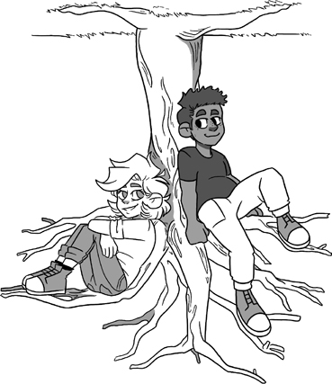

程序需要定义自己的数据结构。一种实用而优雅的方式，是使用*数据类型*。它们定义数据可以具有的形状，即*变体*，以及每个变体携带的值，即*载荷*。例如，表示咖啡馆产品的数据类型，可以有MatchaTea和Latte两个变体，而Latte的载荷可以是一个描述浓缩咖啡份数的整数。Programs have a need to define their own data structures. A useful and elegant way to do that is to use *datatypes*. These define what shapes, or *variants*, data can have and the values, or *payload*, that each variant carries. For example, a datatype representing coffee-shop products may have the variants MatchaTea and Latte, and the payload of Latte may be an integer describing a number of shots of espresso.

数据类型描述不可变的*值*（而不是第16章和第17章中类所描述的可变*状态*）。这使它们不仅适合代码，也适合规约和证明。由于这种数学形式，数据类型有时称为*代数数据类型*。A datatype describes immutable *values* (not mutable *state*, as the classes we'll study in Chapters 16 and 17 do). This makes them well-suited not just in code, but also in specifications and proofs. Because of this mathematical form, datatypes are sometimes called *algebraic datatypes*.

数据类型通常以递归方式定义。也就是说，可以用简单变体，或用包含其他数据类型的变体构建值。因此，它们被称为*归纳数据类型*。Datatypes are often defined recursively. That is, values can be built up from simple variants or from variants that contain other datatypes. For this reason, they are known as *inductive datatypes*.

## 4.0. 蓝黄树4.0. Blue-Yellow Trees

数据类型定义其值的可能结构，并将其划分为不同的*变体*。例如，考虑一种二叉树结构，每个叶结点不是蓝色就是黄色。这样的蓝黄树有三种变体：蓝色叶结点是一棵蓝黄树，黄色叶结点是一棵蓝黄树，而带有两棵子树（即两个本身也是蓝黄树的分量）的内部结点也是一棵蓝黄树。下图展示蓝黄树的三种形式：A datatype defines the possible structure of its values, divided into different *variants*. As an example, let us consider a binary tree structure where each leaf node is either blue or yellow. There are three variants of such blue-yellow trees: a blue leaf node is a blue-yellow tree, a yellow leaf node is a blue-yellow tree, and an interior node with two subtrees (that is, with two components that are themselves blue-yellow trees) is a blue-yellow tree. Here is a pictorial view of the three forms of blue-yellow trees:

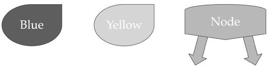

在程序文本中，将此数据类型命名为BYTree，声明如下：In the program text, this datatype, call it BYTree, is declared as follows:

**datatype** BYTree = BlueLeaf | YellowLeaf | Node(BYTree, BYTree)

=右侧描述了能够构造出的BYTree的*所有可能变体*。这是数据类型的一项重要性质。它意味着，即使持有一个未知的数据类型值，仍然知道它是该类型声明中的某个变体。每个变体都有具名的*构造器*。构造器用|分隔，列出顺序无关紧要。The right-hand side of the = describes *every possible variant* of a BYTree that can be constructed. This is an important property of a datatype. It means that if you have an unknown value of a datatype, you still know it is one of the variants declared in the type. Each variant has a named *constructor*. The constructors are separated by |'s and the order in which they are listed is immaterial.

在这个例子中，BlueLeaf和YellowLeaf是无参数构造器，Node则接收两个实参。对于无参数构造器，Dafny允许省略括号()。这里Node的实参类型本身就是BYTree，但一般而言，构造器实参的类型并不限于正在定义的类型。In the example, BlueLeaf and YellowLeaf are parameter-less constructors, and Node is a constructor that takes two arguments. Dafny allows us to leave off the parentheses () for parameter-less constructors. In this example, the types of Node's arguments are themselves BYTree, but in general, the types of constructor arguments are not limited to the type being defined.

构造器像函数一样使用（无参数时则像常量），因此表达式The constructors are used as functions (or, in the parameter-less case, as constants), so the expression

Node(BlueLeaf, Node(YellowLeaf, BlueLeaf))

表示下面这棵树：denotes the tree

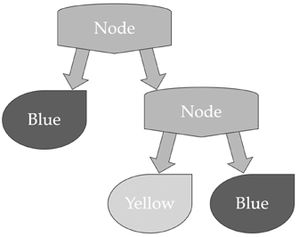

## 4.1. 数据类型的匹配4.1. Matching on Datatypes

在数据类型上定义函数时，通常根据给定数据类型值的变体，确定函数值。用match表达式最容易做到。为说明起见，考虑一个统计给定蓝黄树中蓝色结点数量的函数：When we define a function on a datatype, it is typical to determine the value of the function based on the variant of the given datatype value. This is most easily done using a match expression. To illustrate, consider a function that counts the number of blue nodes in a given blue-yellow tree:

**function** BlueCount(t: BYTree): **nat** {

**match** t

**case** BlueLeaf => 1

**case** YellowLeaf => 0

**case** Node(left, right) => BlueCount(left) + BlueCount(right)

}

**match**表达式接收一个源表达式（本例中为t），后面跟若干**case**分支。每个**case**给出一种*模式*，**match**表达式的求值结果，是源表达式所匹配的**case**中=>之后的表达式。模式是一个数据类型构造器，其参数（如果有）由绑定变量或嵌套模式给出。绑定变量（本例Node分支中的left和right）会绑定到构造Node时传入的参数值。绑定变量的作用域，是其声明所在模式对应的**case**主体。A **match** expression takes a source expression (t in this case) followed by a number of **case** branches. Each **case** gives a *pattern*, and the **match** expression evaluates to the expression that follows the => of the **case** that the source expression matches. A pattern is a datatype constructor whose parameters (if any) are given by bound variables or by nested patterns. The bound variables (left and right in the Node case of the example) get bound to the values that had parameterized the Node when it was constructed. The scope of the bound variables is the body of the **case** in whose pattern they are declared.

对于执行到**match**表达式时源表达式可能具有的每个值，**match**表达式都必须包含相应的**case**。各分支按顺序匹配。A **match** expression must include a **case** for each possible value that the source expression can have when the **match** expression is reached. The cases are matched in order.

## 习题4.0。Exercise 4.0.

如果删除函数BlueCount中的**case** Yellow => 0一行，会发生什么？What happens if you delete the line **case** Yellow => 0 in function BlueCount?

如果模式中的绑定变量未在相应**case**主体中使用，可以将它写为_。例如，以下函数计算树最左分支的长度：If the bound variable in a pattern is not used in the corresponding **case** body, it can be given as _. For example, here is a function that computes the length of a tree's leftmost spine:

**function** LeftDepth(t: BYTree): **nat** {

**match** t

**case** BlueLeaf => 0

**case** YellowLeaf => 0

**case** Node(left, _) => 1 + LeftDepth(left)

}

由于该函数不需要Node的第二个参数，Node模式用下划线代替了该参数的名称。Since this function does not need the second parameter of the Node, the Node pattern uses an underscore instead of naming the parameter.

## 习题4.1。Exercise 4.1.

编写函数ReverseColors，接收一棵蓝黄树，返回一棵与之相同的树，但将蓝色结点变成黄色结点，将黄色结点变成蓝色结点。Write a function ReverseColors that takes a blue-yellow tree and returns a tree just like it, except with blue nodes turned into yellow nodes and yellow nodes turned into blue nodes.

## 习题4.2。Exercise 4.2.

程序验证器通常用于证明程序对所有输入都按预期运行。但也可以用它*测试*函数对于一些简单输入是否符合预期。例如，以下方法调用习题4.1的ReverseColors，用**assert**语句检查函数对两个输入的行为是否符合预期：A program verifier is typically used to prove that a program behaves as expected for all inputs. But you can also use it to *test* that a function behaves as expected for some simple inputs. For example, the following method calls ReverseColors from Exercise 4.1 and uses **assert** statements to check that the function behaves as expected for two inputs:

**method** TestReverseColors() {

**var** a := Node(BlueLeaf, Node(BlueLeaf, YellowLeaf));

**var** b := Node(YellowLeaf, Node(YellowLeaf, BlueLeaf));

**assert** ReverseColors(a) == b;

**assert** ReverseColors(b) == a;

}

本书后面会看到更多这样的测试框架。再为ReverseColors编写三个简单测试用例。另外，编写一个“负面测试”，即你预期会失败的测试。We'll see more test harnesses like this later in the book. Write three more simple test cases for ReverseColors. Also, write a “negative test”—a test that you expect to fail.

## 习题4.3。Exercise 4.3.

编写函数Oceanize，接收一棵蓝黄树，返回一棵与之相同的树，但把所有叶结点变成蓝色叶结点。Write a function Oceanize that takes a blue-yellow tree and returns a tree just like it, except with all leaf nodes turned into blue leaf nodes.

## 4.2. 判别器与解构器4.2. Discriminators and Destructors

有时，我们想知道数据类型值属于哪个变体，也就是想知道用哪个构造器创建了该值。可以编写函数来判断。下面的函数IsNode在给定数据类型值由Node构造器构造时返回**true**：Sometimes, we want to know the variant of a datatype value. That is, we want to know which constructor was used to create the value. We can write a function to determine this. Here is a function IsNode that returns **true** if the given datatype was constructed using the Node constructor:

**predicate** IsNode(t: BYTree) {

**match** t

**case** BlueLeaf => **false**

**case** YellowLeaf => **false**

**case** Node(_, _) => **true**

}

（请记住，**predicate**只是结果类型为**bool**的**function**。）(Remember that a **predicate** is simply a **function** with result type **bool**.)

由于IsNode是常用操作，Dafny为每个构造器预定义了这样的*判别器*。判别器名称就是构造器名称后加一个问号，因此类型BYTree的判别器名称是BlueLeaf?、YellowLeaf?和Node?。判别器是该类型的*成员*，因此访问时，要在表达式之后加上点号和成员名称。对于BYTree类型的表达式t，上面定义的谓词IsNode以IsNode(t)方式调用，而判别器以t.Node?方式调用。注意，对于BlueLeaf这样的无参数构造器，表达式t.BlueLeaf?等价于t == BlueLeaf。Since IsNode is a common operation, Dafny pre-defines such a *discriminator* for each constructor. The name of the discriminator is the name of the constructor followed by a question mark, so the names of the discriminators for type BYTree are BlueLeaf?, YellowLeaf?, and Node?. The discriminators are *members* of the type, which means they are accessed by following an expression with a dot and the name of the member. So, whereas the predicate IsNode we defined above is invoked as IsNode(t) for an expression t of type BYTree, a discriminator is invoked as t.Node?. Note, for a parameter-less constructor like BlueLeaf, the expression t.BlueLeaf? is equivalent to t == BlueLeaf.

数据类型上的另一种有用操作，是提取传给构造器的某个参数。例如，以下函数取出Node的第一个参数：Another useful operation on a datatype is to extract one of the parameters passed to a constructor. For example, the following function retrieves the first parameter of a Node:

**function** GetLeft(t: BYTree): BYTree

**requires** t.Node?

{

**match** t

**case** Node(left, _) => left

}

注意，GetLeft的前置条件说明，该函数只能用于Node变体的蓝黄树。这意味着**match**表达式只需考虑一种情况。Note that GetLeft's precondition says the function can only be applied to a blue-yellow tree of the Node variant. This means that the **match** expression only needs to consider one case.

由于GetLeft是常用操作，Dafny提供了一种方便方式，只需为参数命名，就能为构造器的每个参数声明这样的*解构器*。例如，以下数据类型声明为Node的每个实参定义了解构器，分别名为left和right：Since GetLeft is a common operation, Dafny provides a convenient way to declare such a *destructor* for each parameter of a constructor, simply by naming the parameter. For example, the following datatype declaration defines a destructor for each argument to Node, calling them left and right, respectively:

**datatype** BYTree = BlueLeaf

| YellowLeaf

| Node(left: BYTree, right: BYTree)

不必为每个构造器实参都命名解构器，但如果愿意，可以这样做。It is not necessary to name a destructor for every constructor argument, but you can if you like.

与判别器一样，解构器也是数据类型的成员。因此，对于BYTree类型的表达式t，函数GetLeft以GetLeft(t)方式调用，而解构器以t.left方式调用。就像上面为函数GetLeft声明的前置条件一样，解构器自动具有该前置条件。具体而言，t.left的前置条件为t.Node?，因此解构器left只能应用于Node变体的BYTree值。As with discriminators, destructors are members of the datatype. Thus, whereas function GetLeft is invoked by GetLeft(t) for an expression t of type BYTree, a destructor is invoked by t.left. Just like we declared a precondition for function GetLeft above, a destructor automatically gets that precondition. In particular, the precondition of t.left is t.Node?, so the destructor left can be applied only to BYTree values of the Node variant.

注意，可以利用判别器和解构器，为上面的函数BlueCount给出另一种实现：Note that we can use discriminators and destructors in an alternative implementation of function BlueCount from above:

**function** BlueCount(t: BYTree): **nat** {

**if** t.BlueLeaf? **then** 1

**else if** t.YellowLeaf? **then** 0

**else** BlueCount(t.left) + BlueCount(t.right)

}

## 习题4.4。Exercise 4.4.

利用判别器、解构器和一个**if**-**then**-**else**表达式，定义上面的函数LeftDepth。Define function LeftDepth from above in terms of discriminators and destructors and a single **if**-**then**-**else** expression.

## 习题4.5。Exercise 4.5.

考虑两个蓝黄树t和u上的谓词HasLeftTree，它判断t是否为以u作为左子树的内部结点。用两种不同方式实现该函数：一种使用**match**表达式，另一种使用判别器和解构器。如何确保解构器满足其前置条件？Consider a predicate HasLeftTree on two blue-yellow trees, t and u, that determines whether or not t is an internal node with u as its left subtree. Implement this function in two different ways, one using a **match** expression and one using a discriminator and destructor. How do you make sure the destructor meets its precondition?

## 4.3. 结构包含4.3. Structural Inclusion

数据类型通常以递归方式定义。上面已经见过，BYTree的Node构造器本身接收BYTree类型的实参。因此，数据类型上的函数也往往是递归的。上面也见过，函数BlueCount和LeftDepth都是递归定义的。如何确信这些递归会终止？Datatypes are often defined recursively. We saw this above, where BYTree's Node constructor itself takes arguments of type BYTree. Consequently, functions on datatypes are often recursive as well. We saw this above, too, where functions BlueCount and LeftDepth were defined recursively. How can we be sure this recursion terminates?

归纳数据类型的一项显著性质，是其值可通过有限次构造器调用得到。例如，第4.0节最后描绘的那棵树，可以写成表达式A salient property of inductive datatypes is that their values can be obtained by a finite number of constructor invocations. For example, the last tree depicted in Section 4.0 can be written as the expression

Node(BlueLeaf, Node(YellowLeaf, BlueLeaf))

其中用了五次构造器调用。我们说，传给数据类型构造器的数据类型参数，在结果中*被结构包含*。由于归纳数据类型的有限性，这种结构包含是一种良基关系。例如，对于任意BYTree类型的值t和u，有：which uses five constructor invocations. We say that the datatype parameters passed to a datatype constructor are *structurally included* in the result. By the finiteness of inductive datatypes, this structural inclusion is a well-founded relation. For example, for any values t and u of type BYTree, we have:

Node(t, u) ≻ t

以及and

Node(t, u) ≻ u

结构包含是Dafny中归纳数据类型内置的良基序。例如，证明上面BlueCount和LeftDepth终止的**decreases**子句是**decreases** t。由于t是这些函数唯一的参数，如果没有显式给出，Dafny就默认使用这个**decreases**子句（参见第3.4节），这解释了为何上述例子不会产生关于终止性的异议。Structural inclusion is the built-in well-founded order on inductive datatypes in Dafny. For example, the **decreases** clause that proves termination of both BlueCount and LeftDepth above is **decreases** t. Since t is the single parameter of these functions, Dafny defaults to this **decreases** clause if none is supplied explicitly (see Section 3.4), which explains why the examples above did not produce any complaints about termination.

## 4.4. 枚举4.4. Enumerations

假设要定义叶结点不止有蓝色和黄色的树。可以添加更多构造器，如GreenLeaf和RedLeaf。另一种做法是，只用Leaf和Node两个构造器声明树数据类型，并给Leaf传入一个颜色参数：Suppose we want to define trees whose leaf nodes can be of more colors than just blue and yellow. We could then add further constructors, like GreenLeaf and RedLeaf. Alternatively, we can declare a tree datatype with just two constructors, Leaf and Node, and parameterize Leaf with a color:

**datatype** ColoredTree = Leaf(Color)

| Node(ColoredTree, ColoredTree)

如果颜色来自固定的一组可能颜色，就可以用数据类型定义可能的颜色变体。例如：If the color comes from a fixed set of possible colors, then we can use a datatype to define the possible color variants. For example:

**datatype** Color = Blue | Yellow | Green | Red

在这种每个构造器都无参数的特殊情况下，我们称该数据类型为*枚举*。In this special case where every constructor is parameter-less, we say that the datatype is an *enumeration*.

正如预期，可以在枚举上定义函数，例如As expected, we can define functions on enumerations, like

**predicate** IsSwedishFlagColor(c: Color) {

c.Blue? || c.Yellow?

}

**predicate** IsLithuanianFlagColor(c: Color) {

c != Blue

}

## 习题4.6。Exercise 4.6.

在彩色树上定义谓词IsSwedishColoredTree，判断所有叶结点的颜色是否也都出现在瑞典国旗上。Define a predicate IsSwedishColoredTree on colored trees that determines whether or not all leaves have colors that also appear in the Swedish flag.

## 4.5. 类型参数4.5. Type Parameters

到目前为止，已经见过蓝黄树和彩色树两种树。不难想象，我们还会需要许多其他种类的树，它们都共享基本的叶结点和内部结点结构。为此，希望用载荷的类型，也就是树中所存数据的类型，来参数化树的定义。By now, we have already seen two kinds of trees, blue-yellow trees and colored trees. It is not hard to imagine that we will want to have many other kinds of trees as well, all of which share the basic leaf/node structure. For this purpose, we want to parameterize the definition of a tree with the type of its payload, that is, the data stored in the tree.

下面是一般二叉树的定义。它接收类型T作为参数：Here is a definition of general binary trees. It takes a type T as a parameter:

**datatype** Tree<T> = Leaf(data: T)

| Node(left: Tree<T>, right: Tree<T>)

这个声明定义了整个树族，每种可能的类型T对应一种树。例如，以Color参数化Tree，写成Tree<Color>，表示与上面ColoredTree相似的类型。不过，我们通常仍把Tree（不带参数实例化）当作一个类型来思考和谈论。接收类型参数的类型通常称为*泛型类型*。This declaration defines a whole family each trees, one for each possible type T. For example, by parameterizing Tree with Color, written Tree<Color>, we denote a type that is similar to ColoredTree above. However, we typically think and speak of Tree (without a parameter instantiation) as one type. A type that takes type parameters is often called a *generic type*.

当然，可以在某个具体树类型上定义函数，例如We can, of course, define a function on a specific tree type, like

**predicate** AllBlue(t: Tree<Color>) {

**match** t

**case** Leaf(c) => c == Blue

**case** Node(left, right) => AllBlue(left) && AllBlue(right)

}

这个函数只能应用于Tree<Color>类型的值。也可以用类型来参数化函数，从而在Tree族中的任意类型上定义函数。下面的函数Size以类型T和Tree<T>类型的值t为参数，返回t中的叶结点数：This function can be applied only to values of the type Tree<Color>. We can also parameterize a function by a type. This lets us define the function on any type in the family Tree. Here is a function Size, parameterized by a type T and a value t of type Tree<T>, that returns the number of leaf nodes in t:

**function** Size<T>(t: Tree<T>): **nat** {

**match** t

**case** Leaf(_) => 1

**case** Node(left, right) => Size<T>(left) + Size<T>(right)

}

调用函数时，类型实参通常可以推断。如果可以，就能从程序文本中省略它们及其尖括号。例如，更常见的Size定义如下：When calling a function, the type arguments can usually be inferred. If so, we can omit them (along with the angle brackets) from the program text. For example, it would be more common for us to define Size as follows:

**function** Size<T>(t: Tree<T>): **nat** {

**match** t

**case** Leaf(_) => 1

**case** Node(left, right) => Size(left) + Size(right)

}

## 习题4.7。Exercise 4.7.

定义函数Mirror，返回给定树的镜像。Define a function Mirror that returns the mirror image of a given tree.

## 4.6. 表达式的抽象语法树4.6. Abstract Syntax Trees for Expressions

本章最后一个例子，为(5 + 3) * 2和10 * (x + 7 * y)这样的简单算术表达式定义*抽象语法树*（AST）。每个编译器都会使用这样的数据结构。该例说明相互递归，还定义了常用类型List，后面许多例子都会使用它。The final example in this chapter defines an *abstract syntax tree* (AST) of simple arithmetic expressions like (5 + 3) * 2 and 10 * (x + 7 * y). Such data structures are used in every compiler. The example illustrates mutual recursion, and it also defines the common type List that we will use in many examples to come.

在这个例子中，表达式有三种变体：字面常量、变量和运算。相应的数据类型Expr为For the example, expressions have three variants: literal constants, variables, and operations. The corresponding datatype, Expr, is

**datatype** Expr = Const(**nat**)

| Var(**string**)

| Node(op: Op, args: List<Expr>)

构造器Const的参数是所表示的数字字面量。Var的参数是变量名称。构造器Node接收一个运算，在这个简单例子中，将它定义为以下运算之一：The parameter to the constructor Const is the numeric literal being represented. The parameter to Var is the name of the variable. Constructor Node takes an operation, which in this simple example I define to be one of the following:

**datatype** Op = Add | Mul

以及一个包含任意多个Expr实参的列表。and a list of (any number of) Expr arguments.

泛型类型List定义如下：The generic type List is defined as follows:

**datatype** List<T> = Nil | Cons(head: T, tail: List<T>)

这里使用常见名称Nil表示空列表，Cons表示非空列表。非空列表有两个分量：携带载荷的head，以及表示列表其余部分的tail。This uses the common names Nil to denote an empty list and Cons to denote a nonempty list. A nonempty list has two components, the head, which carries the payload, and tail, which denotes the rest of the list.

例如，算术表达式10 * (x + 7 * y)表示为As an example, the arithmetic expression 10 * (x + 7 * y) is represented by

Node(Mul,

Cons(Const(10),

Cons(Node(Add,

Cons(Var("x"),

Cons(Node(Mul,

Cons(Const(7),

Cons(Var("y"),

Nil))),

Nil))),

Nil)))

来为这些表达式定义一个简单解释器。它计算给定表达式的值。由于变量值依赖于某个*环境*，我们让求值函数接收从变量名到值的*映射*。Let's define a simple interpreter for our expressions. It computes the value of a given expression. Since the value of a variable depends on some *environment*, we let the evaluation function take a *map* from variable names to values.

**function** Eval(e: Expr, env: **map**<**string**, **nat**>): **nat** {

**match** e

**case** Const(c) => c

**case** Var(s) => **if** s **in** env.Keys **then** env[s] **else** 0

**case** Node(op, args) => EvalList(args, op, env)

}

**function** EvalList(args: List<Expr>, op: Op,

env: **map**<**string**, **nat**>): **nat**

{

**match** args

**case** Nil =>

(**match** op **case** Add => 0 **case** Mul => 1)

**case** Cons(e, tail) =>

**var** v0, v1 := Eval(e, env), EvalList(tail, op, env);

**match** op

**case** Add => v0 + v1

**case** Mul => v0 * v1

}

有四点需要说明。Four remarks are in order.

第一，后面会看到许多使用映射等集合类类型的例子。对于本例，只需知道：**map**<A, B>类型的映射，将有限多个A值分别关联到一个B值。前者称为映射的*键*，后者称为映射的*值*。映射的键集合通过.Keys成员取得。因此，表达式a **in** m.Keys告诉你a是否为m的键。对于已知是m的键的a，表达式m[a]给出m与键a关联的B值。First, we will see many examples with collections such a maps later. For this example, it suﬃces to know that a map of type **map**<A, B> associates with each of a finite number of A values a B value. The former are called the *keys* of the map and the latter are called the *values* of the map. The set of keys of the map is retrieved using the .Keys member. So the expression a **in** m.Keys tells you whether or not a is a key of m. For an a known to be a key of m, the expression m[a] yields the B value that m associates with the key a.

我选择让Eval方法适用于任意给定环境，即使环境没有为给定表达式提及的每个变量提供映射也可以。如果表达式中的某个变量名在环境中没有映射，Eval就使用0作为默认值。另一种做法是，为Eval设定前置条件，要求给定环境为给定表达式提及的每个变量都提供映射，参见习题4.9和4.10。I chose to make our method Eval work on any given environment, even one that does not contain a mapping for every variable mentioned in the given expression. If a variable name in the expression is not mapped by the environment, Eval uses 0 as a default value. An alternative would be to require as a precondition of Eval that the given environment has a mapping for every variable mentioned in the given expression, see Exercises 4.9 and 4.10.

第二，EvalList的Cons分支使用局部变量绑定，为递归调用Eval和EvalList的结果引入名称。它们本可以写成Second, the Cons case of EvalList uses local variable bindings to introduce names for the results of the recursive calls to Eval and EvalList. These could have been written as

**var** v0 := Eval(e, env);

**var** v1 := EvalList(tail, op, env);

但我选择将它们写成同时赋值。使用两次独立赋值，还是一次同时赋值，属于风格选择；不过，后者当然只有在绑定发生之前就能求出右侧表达式时才可行（换句话说，v0没有出现在v1的右侧表达式中，反之亦然）。在**match**构造中，某个**case**引入的变量，在该**case**结束时就离开作用域。but instead, I chose to write them as a simultaneous assignment. Choosing between two separate assignments and one simultaneous assignment is a matter of style, though the latter is of course possible only if the right-hand sides can be evaluated before the bindings take place (in other words, if v0 is not used in the right-hand side for v1 and vice versa). In a **match** construct, any variable introduced in one **case** goes out of scope at the end of that **case**.

表达式中的**var**绑定器通常称为*let表达式*。这个名称来自函数式语言中常见的语法A **var** binder in an expression is usually called a *let expression*. This name comes the common functional-languages syntax

**let** x = E **in** F // not Dafny syntax

它对表达式E求值，将结果绑定到变量x，然后对可能提及x的F求值，作为整个表达式的结果。如刚才所见，Dafny中这种let表达式的语法为which evaluates expression E, binds the result to variable x, and then results in the evaluation of F, which may mention x. As we just saw, the syntax for such a let-expression in Dafny is

**var** x := E; F // Dafny syntax, which can be pronounced as

// "let x be E in F"

它刻意设计得与引入局部变量的对应语句形式相似。which is made to look like the statement counterpart that introduces local variables.

第三，注意第一个嵌套**match**表达式需要括号包围，否则**case** Cons(e, tail)会被解析为**match** op的第三个分支。相比之下，第二个嵌套**match**不需要额外括号，因为剩余所有**case**都属于它。在语法上，Dafny允许用花括号将一个**match**的所有**case**组合在一起；因此，除了写成（**match** op …），也可以写成Third, note that the first nested **match** expression requires enclosing parentheses, or else **case** Cons(e, tail) would be parsed as a third case of the **match** op. In contrast, note that the second nested **match** does not need more parentheses, since all remaining **case**'s belong to it. Syntactically, Dafny allows the use of curly braces to group together all **case**'s of a **match**; so as an alternative to writing (**match** op …), one can write

**match** op {

**case** Add => 0

**case** Mul => 1

}

注意花括号的位置，与包围表达式的圆括号位置有何不同。Note the placement of the curly braces, compared to the placement of the enclosing round parentheses.

第四，函数Eval和EvalList相互递归。终止性成立，是因为数据类型实参——Eval的e，以及EvalList的args——在每次（相互）递归调用中都在结构上变小。也就是说，终止性证明的关键要素为Fourth, the functions Eval and EvalList are mutually recursive. Termination follows, because the datatype argument, e for Eval and args and EvalList, are structurally smaller for every (mutually) recursive call. That is, the essential ingredients of the proof of termination are

Node(op, args) ≻ args

Cons(e, tail) ≻ e

Cons(e, tail) ≻ tail

由于这些参数恰好列在函数签名首位，Dafny默认的**decreases**子句足以让验证器检查终止性。Since these parameters happen to be listed first in the function signatures, Dafny's default **decreases** clauses suﬃce for the verifier to check termination.

## 习题4.8。Exercise 4.8.

修改函数EvalList的签名，使参数op: Op位于参数args: List<Expr>之前。这会导致Dafny发出无法证明终止性的错误消息。为什么？为EvalList编写显式的**decreases**子句来解决问题。Change the signature of function EvalList so that parameter op: Op precedes parameter args: List<Expr>. This will cause Dafny to emit an error about not being able to prove termination. Why? Solve this problem by writing an explicit **decreases** clause for EvalList.

## 习题4.9。Exercise 4.9.

编写谓词GoodEnv(e: Expr, env: **map**<**string**, **nat**>)，使它在env的键包含e提及的全部变量名时成立。为此，还需要编写一个类似的辅助谓词，处理的不是单个表达式e，而是表达式列表。Write a predicate GoodEnv(e: Expr, env: **map**<**string**, **nat**>) that holds whenever the keys of env include all the variable names mentioned in e. This will also require writing a similar, auxiliary predicate for not just one expression e, but for a list of expressions.

## 习题4.10。Exercise 4.10.

将函数Eval的Var分支改为仅仅env[s]。利用习题4.9中的谓词，添加必要前置条件，使Eval和EvalList通过验证。Change the Var case of function Eval to be simply env[s]. Using the predicates developed in Exercise 4.9, add the necessary preconditions to make Eval and EvalList verify.

## 4.7. 小结4.7. Summary

数据类型提供了定义一组值的方法。数据类型的值被划分为一组固定的变体，每个变体都有一个构造器。构造器像函数一样，可以接收参数。它是一种特殊函数，因为它具有*单射性*，这意味着能够从构造器产生的值中，还原传给构造器的参数。这种解构通常通过**match**语句或**match**表达式完成，也可以组合使用判别器和解构器完成。A datatype gives a way to define a set of values. The values of a datatype are partitioned into a fixed set of variants. The datatype has one constructor for each variant. The constructor is like a function in that it can take parameters. It is a special function, because it is *injective*, which means that it is possible to recover the parameters passed to the constructor from the value produced by the constructor. This deconstruction is commonly done with a **match** statement or **match** expression, but can also be done using a combination of discriminators and destructors.

我将这些数据类型称为“归纳的”。这实质上意味着，它们的每个值都是用有限步骤自底向上构造的。构造器产生的值，被称为在结构上包含作为参数传给该构造器的任何数据类型值。由于数据类型值的结构有限，这种结构包含是良基的。I've referred to the datatypes as “inductive”. This essentially means that each of their values is constructed bottom-up using a finite number of steps. A value that is produced by a constructor is said to structurally include any datatype values passed in as parameters to the constructor. Because of the finite structure of datatype values, this structural inclusion is well-founded.

下一章将探讨数学归纳法，即依据较小的证明来编写证明的方法。这与归纳数据类型颇为相似。事实上，证明归纳数据类型的性质时，几乎总要使用数学归纳法，但数学归纳法也有许多其他应用。In the next chapter, we'll explore mathematical induction, which is a way to write proofs in terms of smaller proofs. This is not unlike inductive datatypes. Indeed, to prove properties of inductive datatypes, you almost always use mathematical induction, but there are also many other applications of mathematical induction.

## 注记Notes

归纳数据类型是所有基于函数式编程的语言和验证器的基本要素。例如，类型Tree的定义在F*中写成Inductive datatypes are the bread and butter of all languages and verifiers based on functional programming. For example, the definition of type Tree is written

**type** tree (t:Type) : Type =

| Leaf : data:t -> tree t

| Node : left:tree t -> right:tree t -> tree t

上述形式[53]。大多数命令式语言都支持枚举，即构造器不接收任何参数的数据类型。Scala、Rust、Java和C#等语言也能使用载荷，但由于这些语言暴露了此类值在内存中分配的细节，因此在规约和验证中更难使用它们。in F* [53]. Enumerations (that is, datatypes where the constructors don't take any parameters) are supported by most imperative languages. The use of payloads is also possible in languages like Scala, Rust, Java, and C#, but because these languages expose details of the allocation of such values in memory, they are harder to use in specification and verification.

本章介绍的数据类型是归纳的，这意味着其结构有限。例如，如果不断沿BYTree的左分支前进，最终一定会到达叶结点。虽然远不如归纳数据类型常见，但也存在*共归纳数据类型*，其值可以具有无限结构。初看起来，对于程序要在计算机有限内存中执行的编程语言，这样的值似乎不可行。但通过*惰性*求值，可以表示无限结构的有限部分。这可以带来优美的程序写法，也是Haskell编程语言的一项鲜明特色[110]。原型编程语言Charity强调归纳与共归纳数据类型的对偶性[28]。共归纳数据类型还可以用于规约，描述某些程序的行为。例如，可以用共归纳数据类型表示Web服务器不断处理的无尽请求流。Dafny、Liquid-Haskell[86]和Agda[22]都支持共归纳数据类型，但证明这类程序的性质属于高级主题，超出本书范围。The datatypes introduced in this chapter are inductive, which implies their structure is finite. For example, if you keep following the left branch of a BYTree, you will eventually get to a leaf. Although much less common, there are also *coinductive datatypes*, whose values can have an infinite structure. At first, it may seem that such values are infeasible for a programming language whose programs will execute in a computer's finite memory. But by evaluating these structures *lazily*, one can represent finite portions of the infinite structures. This can lead to beautiful renditions of programs, a hallmark of the Haskell programming language [110]. The duality of inductive and coinductive datatypes is emphasized is the prototype programming language Charity [28]. Coinductive datatypes can also be used in specifications to describe the behavior of some programs. For example, you can use a coinductive datatype to represent an endless stream of requests being processed by a web server. Dafny, Liquid-Haskell [86], and Agda [22] support coinductive datatypes, but proving properties of such programs is an advanced topic beyond the scope of this book.

# 第5章 引理与证明Chapter 5 Lemmas and Proofs

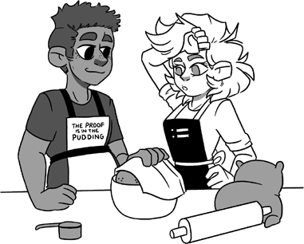

对程序进行推理时，我们经常需要手工编写部分证明。当这样的证明很长，或想在多处复用同一个证明时，就为正在证明的性质命名。这通过*引理*来完成，可以把它看作较大证明中的子例程。As we reason about programs, we often need to write some parts of the proofs manually. When such a proof is long or when we want to reuse the same proof in multiple places, we give the property we're proving a name. This is done by a *lemma*, which you can think of as a subroutine in a larger proof.

本章重点是编写和证明引理。这是程序推理中一切工作的核心。我们将看到证明与Floyd逻辑之间的紧密联系，学习归纳法，并编写证明演算。尤其重要的是，你还会开始了解：当验证器指出无法证明程序时，如何与它交互。This chapter focuses on writing and proving lemmas. It is central to everything we do when reasoning about programs. We'll see that there is a strong link between proofs and Floyd logic, we'll learn about induction, and we'll be writing proof calculations. Crucially, you'll also start to see how to interact with the verifier when it complains that it cannot prove your program.

证明引理时所做的思考和调试，与证明程序正确时相同。因此，练习编写证明的技能，会让你具备推理更困难程序的本领。熟练编写证明后，你就能够思考程序中有趣的方面，而不是把时间花在琢磨如何诊断失败的证明尝试上。The thinking and debugging you do when proving a lemma is the same as when proving programs correct. Therefore, practicing the skills of writing proofs gives you the chops to reason about more diﬃcult programs. When you're comfortable writing proofs, you'll be able to think about the interesting aspects of your programs instead of spending your time wondering how to diagnose failed proof attempts.

## 5.0. 声明引理5.0. Declaring a Lemma

为了说明为何需要引理，先从一个简单例子开始。考虑以下函数，它总是返回比实参大的值：To illustrate the need for lemmas, let me start with a simple example. Consider the following function, which always returns something larger than its argument:

**function** More(x: **int**): **int** {

**if** x <= 0 **then** 1 **else** More(x - 2) + 3

}

我说More“总是返回比实参大的值”。真的是这样吗？如何确信？如果你刚才在头脑中思考过，就会考虑两种情形，正如函数体有两个分支。第一种，当x不大于0时，很容易看出More(x)返回1，确实大于这样的x。另一种，当x严格为正时，你或许想到不断展开递归调用，直到适用第一种情形。函数给每次递归调用的结果加3，因此如果正确计算递归调用次数，或许就能确信，或者至少觉得合理：More(x)总是返回比x大的值。I said More “always returns something larger than its argument”. Does it? How can we be sure of that? If you thought about this in your head just now, you would be considering two cases, just like the body of the function has two cases. In one case, when x is no greater than 0, it is easy to see that More(x) returns 1, which is indeed larger than such an x. In the other case, when x is strictly positive, perhaps you thought about the repeated unwinding of recursive calls until the first case applies. The function adds 3 to the result of each recursive call, so if we count the recursive calls correctly, maybe we can convince ourselves, or at least find it plausible, that More(x) always returns something greater than x.

稍后会证明More的这个性质（在第5.2节）。现在，先考虑如何写下性质本身。做法如下，我将这个性质命名为Increasing：We'll prove this property about More later (in Section 5.2). For now, let's just think about how to write down the property itself. Here's how you do that, where I've given the property the name Increasing:

**lemma** Increasing(x: **int**)

**ensures** x < More(x)

*引理*（有些人称为*定理*）是具有证明的数学断言。在Dafny中，引理很像方法：它有名称，可以带参数，有前置条件和后置条件，也可以被调用。引理提出的逻辑断言由后置条件声明。正如方法调用者在调用终止时获知后置条件，引理调用者也会获知引理提出的逻辑断言。对引理适用条件的任何限制，由其前置条件声明，也与方法一样。A *lemma*, or some would call it a *theorem*, is a mathematical assertion that has a proof. In Dafny, a lemma is very much like a method: it has a name, it can be parameterized, it has a pre- and postcondition, and it can be called. The logical assertion made by the lemma is declared by the postcondition. Just like the caller of a method learns the postcondition upon termination of the call, so the caller of a lemma learns the logical assertion made by the lemma. Any restrictions on when the lemma can be applied are declared by the precondition of the lemma, again just as for methods.

不过，方法与引理确有区别：引理绝不会被编译成供运行时使用的代码，而只由验证器使用，像幽灵构造一样。事实上，在Dafny中，引理*就是*幽灵方法。这意味着你已经知道如何声明、使用，以及——没错——*证明*引理。但把引理视为具名数学断言之后，这些方面都值得再解释一遍。Well, there is a difference between methods and lemmas: a lemma is never compiled into code for use at run time. Instead, the lemma is used only by the verifier, like a ghost construct. In fact, in Dafny, a lemma *is* simply a ghost method. This means you already know how to declare, use, and—yes—*prove* lemmas. But all of these things are worthy of explanation again, thinking of the lemmas as named mathematical assertions.

## 5.1. 使用引理5.1. Using a Lemma

来看一个说明这个引理用法的例子。下面的方法两次调用More：Let's consider an example that illustrates the use of this lemma. The following method makes two calls to More:

**method** ExampleLemmaUse(a: **int**) {

**var** b := More(a);

**var** c := More(b);

**assert** 2 <= c - a;

}

这个示例方法将More(More(a))计算到局部变量c，然后断言c与a之差至少为2。如果More总是返回比实参大的值，那么More(a)返回的值就大于a，即至少为a+1。第二次More调用以第一次调用的结果为实参，因此预期其结果至少为a+2。但验证器指出断言可能不成立。原因是验证器对More的了解不足。具体而言，它需要第5.0节中作为引理陈述的Increasing性质。The example method computes More(More(a)) into local variable c and then asserts that the difference between c and a is at least 2. If More always returns something greater than its argument, then More(a) returns something greater than a, that is, at least a+1. The second call to More is invoked on the result of the first call, so we expect its result to be at least a+2. But the verifier complains that the assertion may not hold. The reason is that the verifier does not know enough about More. In particular, it needs the Increasing property that we stated as a lemma in Section 5.0.

为了证明ExampleLemmaUse中的断言，调用Increasing引理。需要两次引理调用，因为对于a和More(a)，都需要More的性质。To prove the assertion in ExampleLemmaUse, we invoke the Increasing lemma. We need two calls to the lemma, since we need the More property for both a and More(a).

**method** ExampleLemmaUse(a: **int**)

{ ⓪

**var** b := More(a); ①

Increasing(a); ②

Increasing(b); ③

**var** c := More(b); ④

**assert** 2 <= c - a; ⑤

}

现在，断言通过验证了。🙂Now the assertion verifies. 🙂

值得仅在这一次极其详尽地走过例子，看看程序正确性与引理如何联系。来考虑方法每一步的已知信息。It is worthwhile, just this once, to go through the example in excruciating detail so we can see how program correctness and lemmas relate. Let's consider what is known at each step of the method.

- 在⓪，只知道a是整数，它可以是任意整数。At ⓪ , all we know is that a is an integer. It could be any integer.
- 在①，还知道b保存More(a)的值。如果追踪More的定义，可以知道更多；但由于More是递归的，没有归纳证明就走不了太远，而我们还没有做这个证明。At ①, we additionally know that b holds the value of More(a). If we traced through the definition of More, we could learn more, but since More is recursive, we won't get very far without an inductive proof, which we haven't yet done.
- 接下来调用引理Increasing。这意味着有一项证明义务：确立该调用的前置条件。幸运的是，由于Increasing没有声明前置条件，这一点显然成立。因此，调用返回时，在②，获得了调用的后置条件，即a < More(a)。Next up is the call to lemma Increasing. This means there is a proof obligation to establish the precondition of this call. Luckily, since Increasing does not have a declared precondition, this is trivial. Upon return of the call, at ②, we therefore gain the knowledge of the call's postcondition, namely a < More(a).
- 类似地，在③，还获知b < More(b)。由于此时知道b等于More(a)，可以得出 Similarly, at ③, we additionally learn b < More(b). Since we know that b equals More(a) at this point, we can conclude

  More(a) < More(More(a))
- 下一行把局部变量c设为More(b)。由于b的值是More(a)，c的值就是More(More(a))。因此，在④知道以下等式和不等式： In the next line, local variable c is set to More(b). Since the value of b is More(a), the value of c is More(More(a)). Thus, we know the following equality and inequalities at ④:

  a < More(a) < More(More(a)) == c

  由于处理的是整数，这些条件蕴含a + 2 <= c。Since we're dealing with integers, these conditions imply a + 2 <= c.
- 现在，必须根据已知在④成立的条件，证明断言成立。这个断言本身不提供更多信息，因此在⑤的已知信息与④相同。We must now prove that the assertion holds, given what we know to be true at ④. This assertion itself does not give us any more information, so at ⑤ we know the same as what we know at ④.

注意，引理调用与方法调用一样，当然必须在适当时间以正确的值调用。例如，以下代码无法验证断言，因为它对a和More(More(a))调用引理，却从未对More(a)调用：Note that lemma calls are just like method calls in that we need to (of course!) invoke them on the right values and at the right times. For example, the following code does not verify the assertion, since it invokes the lemma on a and More(More(a)), but never on More(a):

**var** b := More(a);

Increasing(a); // this gives us: a < More(a)

**var** c := More(b);

Increasing(c); // here, this gives us:

// More(More(a)) < More(More(More(a)))

**assert** 2 <= c - a; // this assertion cannot be verified here

另一方面，由于引理不修改程序状态，只增加我们对程序状态的了解，可以按相反顺序写出两次引理调用：On the other hand, since the lemma doesn't modify the program state—it only gives us more knowledge about the program state—we can write our two lemma calls in the other order:

**var** b := More(a);

Increasing(b); // this gives us: More(a) < More(More(a))

Increasing(a); // and this gives us: a < More(a)

**var** c := More(b);

**assert** 2 <= c - a; // verifies fine

最后，与调用其他方法一样，通过引理调用获得的信息，只适用于实际调用了该引理的控制路径：Finally, just like calls to other methods, the information gained from a lemma call applies only along the control paths that actually call the lemma:

Increasing(a); // this call is along all control paths

**var** b := More(a);

**var** c := More(b);

**if** a < 1000 {

Increasing(More(a)); // we learn More(a) < More(More(a))

// only here, i.e., when a < 1000

**assert** 2 <= c - a; // this verifies

}

**assert** 2 <= c - a; // this does not verify

上面最后一个断言不能通过验证，因为采取**if**的隐式else分支时，缺少信息More(a) < More(More(a))。The last assertion above does not verify, because we're missing the information More(a) < More(More(a)) when the (implicit) else branch of the **if** is taken.

## 习题5.0。Exercise 5.0.

将上一例子的最后一个断言改为Change the last assertion in the previous example to

**assert** 2 <= c - a || 200 <= a;

会发生什么？为什么？What happens? Why?

## 习题5.1。Exercise 5.1.

方法ExampleLemmaUse引入了两个局部变量b和c。可以不引入c，而是更新b的值，如Method ExampleLemmaUse introduced two local variables, b and c. Instead of introducing c, we could have updated the value of b, as in

b := More(b);

在本节Example-LemmaUse方法体的五种变体中，按这种方式复用b并消除c。是否需要调整断言和引理调用？请说明理由。Reuse b and eliminate c in this way in the five variations of the body of Example-LemmaUse in this section. Do you need to adjust the assertions and lemma calls? Justify.

## 5.2. 证明引理5.2. Proving a Lemma

到目前为止，只声明并使用了引理，还没有证明它。为了证明，需要给引理提供主体。这类似于给方法提供方法体，赋予其实现。因此，没有主体的引理是未经证明的引理，有时称为*猜想*或*公理*。So far, we only declared the lemma and used it, but we never proved it. To prove it, we need to supply the lemma with a body. This is in analogy to how we supply a method with a body to give the method an implementation. A lemma without a body is therefore an unproved lemma, sometimes referred to as a *conjecture* or an *axiom*.

## 边栏5.0Sidebar 5.0

虽然*验证器*愿意接受没有主体的方法（或引理），但*编译器*一旦发现没有主体的方法（或引理）就会报错。事实上，即使编译器会擦除全部幽灵声明，也会先检查是否允许擦除。在此过程中，它会对没有主体的引理报错。在集成开发环境（IDE）中工作时，验证器在后台运行，但编译器不会。因此，直到手动运行编译器，你才会看到关于无主体方法、引理和函数的错误。While the *verifier* is happy to accept a body-less method (or lemma), the *compiler* will complain if it finds a method (or lemma) without a body. In fact, even though the compiler erases all ghost declarations, it will first check that the erasure is permitted. In this process, it will complain about body-less lemmas. When you work in the integrated development environment (IDE), the verifier runs in the background, but the compiler does not. Therefore, you won't see complaints about body-less methods, lemmas, and functions until you (manually) run the compiler.

现在给引理添加主体，拿出花括号吧：It is time to add a body to our lemma, so bring out them curly braces:

**lemma** Increasing(x: **int**)

**ensures** x < More(x)

{

}

如果试一下，你可能会惊讶：验证器*仍然*没有异议。这次，原因是验证器自动证明了引理，不需要你提供其他内容（但*确实*必须给出空主体，否则验证器甚至不会尝试证明）。在幕后，验证器自动应用了一点归纳，而这一点归纳足以证明这个简单引理。这实在太容易了！好吧，之后我们会感激这一点，但这不利于学习证明和归纳。因此，本章余下部分将对每个引理关闭自动归纳。做法是给引理加上属性{:induction **false**}。（也可以更改Dafny IDE设置，在所有地方关闭自动归纳。）If you try this out, you may be surprised that you *still* don't get any complaint from the verifier. This time, the reason is that the verifier proves the lemma automatically, without needing any further input from you (but you *do* have to supply the empty body, or the verifier will not even attempt a proof). Behind the scenes, the verifier automatically applies a smidgen of induction, and this smidgen is enough to prove this simple lemma. This is really too easy! Okay, we'll appreciate this later, but it doesn't help us learn about proofs and induction. Therefore, for the rest of this chapter, we shall turn off the automatic induction for each lemma. This is done by marking the lemma with the attribute {:induction **false**}. (It is also possible to change the settings in the Dafny IDEs to turn off automatic induction everywhere.)

所以，我们从这里开始：So, here's our starting point:

**lemma** {:induction **false**} Increasing(x: **int**)

**ensures** x < More(x)

{

} // the lemma does not verify like this

验证器会报错，因为它无法确认通过方法体的所有控制路径都能确立后置条件。回想第5.0节中的非形式化推理：我们说x <= 0这一情形很容易证明。把这一点明确写进程序文本是个好主意，可以用**if**语句做到：This gives an error from the verifier, because it is unable to confirm that all control paths through the method body lead to the postcondition. Let's recall our informal reasoning from Section 5.0. We said the proof is easy to see for the case when x <= 0. Making this explicit in the program text is a good idea, and we can do that with an **if** statement:

**lemma** {:induction **false**} Increasing(x: **int**)

**ensures** x < More(x)

{

**if** x <= 0 { // this case verifies

} **else** { // this case does not verify yet

}

}

验证器仍然提出异议，但这次只标出了**else**分支：它已经为经过then分支的全部控制路径证明了后置条件。（严格来说，现在庆祝then分支已获证明还太早。验证器通常按程序文本中的顺序考虑控制路径，但不保证如此。）当x <= 0成立时，会采取then分支；在这些情形下，More(x)的定义给出1，因此可以得出x <= 0 < 1 == More(x)。The verifier still responds with a complaint, but this time the complaint only highlights the **else** branch—it has proven the postcondition for all control paths that go through the then branch. (Strictly speaking, it's too early to celebrate having a proof of the then branch. The verifier usually considers controls in the same order as they are given in the program text, but this is not guaranteed.) The then branch is taken when x <= 0 holds; in those cases, the definition of More(x) gives 1; so we can conclude x <= 0 < 1 == More(x).

关于函数More的引理，其**if**条件与函数More定义中的**if**条件相同，这并非偶然。原因是证明通常依赖于正在使用函数定义的哪一部分。一条很好的经验法则是：证明遵循所证明内容的语法结构。It is no accident that the **if** condition in the lemma about function More is the same as the **if** condition in the definition of function More. This is because the proof usually depends on which part of the function's definition is being used. As a good rule of thumb, proofs follow the syntactic structure of what is being proved.

对于引理的else分支，需要更多地帮助验证器。根据定义，当x <= 0不成立时，More(x)等于More(x-2) + 3。因此，证明义务是x < More(x-2) + 3，也就是x-3 < More(x-2)。这个公式的形状与引理中的相同。为了获得这一信息，只需以x-2调用引理：For the else branch of the lemma, we need to help the verifier along more. By definition, More(x) equals More(x-2) + 3 when x <= 0 does not hold. Our proof obligation is therefore x < More(x-2) + 3, which is the same as x-3 < More(x-2). The shape of this formula is the same as that in our lemma. To gain this information, all we need to do is call the lemma on x-2:

**lemma** {:induction **false**} Increasing(x: **int**)

**ensures** x < More(x)

{

**if** x <= 0 {

} **else** {

Increasing(x-2); // this call gives us: x-2 < More(x-2)

}

}

证明至此完成，但别忘了验证器自动处理的一个细节。由于递归调用了引理，需要证明终止性。默认情况下，Dafny采用**decreases** x作为终止性度量（参见第3.4节）；确实，递归调用减小了这个度量。This completes the proof, but let's not forget a detail that the verifier took care of automatically for us. Because the lemma is called recursively, we need to prove termination. By default, Dafny uses **decreases** x as the termination metric (see Section 3.4), and indeed, our recursive call makes this termination metric decrease.

终止性检查很重要，因为它会阻止如下证明尝试：Termination checks are important, because they prevent proof attempts like this one:

**lemma** {:induction **false**} Increasing(x: **int**)

**ensures** x < More(x)

{

Increasing(x); // this would give us x < More(x), but

// the termination check fails

}

这个证明尝试是无效的，原因与第3.0节中试图实现方法Impossible的做法一样：两者都试图通过永不结束的递归调用来达到后置条件。This proof attempt is bogus for the same reason that the attempted implementation of method Impossible in Section 3.0 is—both try to achieve their postcondition with a never-ending recursive call.

## 习题5.2。Exercise 5.2.

按照第5.1节项目列表的详细程度，列明上面最后一个正确版本的引理Increasing中，各程序位置的已知信息。Using the same level of detail as in the bulleted list in Section 5.1, spell out what is known at each program point in the last good version of lemma Increasing above.

递归调用引理，获得了我们正试图证明的性质在规模更小的问题实例上的结论。这称为*归纳*。*归纳原理*指出，证明性质P(x)时，可以自由假设：对于每个小于x的x’，P(x’)都成立。“小于”指第3.2节讨论的良基序中的小于。如果仅将引理视为方法，这一切就归结为证明递归调用终止。不过，按照标准数学术语，我们说递归引理调用获得了*归纳假设*。The recursive call to the lemma obtains the property we're trying to prove for a smaller instance of the problem. This is called *induction*. The *Principle of Induction* says that when proving a property P(x), we are free to assume that P(x’) holds for every x’ that is smaller than x. “Smaller” means smaller in a well-founded order, as discussed in Section 3.2. If you just think of a lemma as a method, it all just comes down to proving termination of recursive calls. Nevertheless, following standard mathematical jargon, we say that recursive lemma calls obtain the *induction hypothesis*.

正如经验法则所说，证明往往遵循所证公式的结构。但它们不必采用相同语法形式。例如，可以颠倒then和else分支顺序，省略空else分支，也可以使用局部变量。下面是引理Increasing的另一种证明：As our rule of thumb says, a proof tends to follow the same structure as the formula that is being proved. They don't need to have the same syntactic form, though. For example, we can reverse the order of then and else branches, we can omit empty else branches, and we can make use of local variables. Here is another proof of lemma Increasing:

**lemma** {:induction **false**} Increasing(x: **int**)

**ensures** x < More(x)

{

**if** 0 < x {

**var** y := x - 2;

Increasing(y);

}

}

## 5.3. 回归基础5.3. Back to Basics

为引理Increasing写出的证明短得令人愉快。它说服了验证器，但如果我们自己仍然不懂呢？或者，你回头看时认可这个证明，却想知道一开始怎样才能想到它。我们来补充更多细节，从简单的Increasing引理开始。The proof we wrote for lemma Increasing is pleasantly short. It convinces the verifier, but what if we still don't get it ourselves? Or perhaps you are convinced by the proof in retrospect, but you're wondering how you would have come up with it in the first place. Let's aim for more details, starting here with the simple Increasing lemma.

### 5.3.0. Floyd逻辑证明5.3.0. Floyd-logic proof

第2章介绍了Floyd逻辑，作为程序推理的基本工具。由于引理证明就是方法实现，Floyd逻辑在此同样适用。用这项技术来构建Increasing的证明吧。I presented Floyd logic in Chapter 2 as the bread and butter for reasoning about programs. Since proofs of lemmas are just implementations of methods, Floyd logic applies equally well here. Let's use that technique to build up the proof of Increasing.

Increasing的整个证明，从引理前置条件（这里是隐式requires true）开始，到引理后置条件（证明目标ensures x < More(x)）结束。因此，使用Hoare三元组记法，将Increasing的主体写成：The overall proof of Increasing starts with the lemma's precondition (here, the implicit requires true) and goes to the lemma's postcondition (the proof goal ensures x < More(x)). Using Hoare-triple notation, we thus write the body of Increasing as follows:

**lemma** {:induction **false**} Increasing(x: **int**)

**ensures** x < More(x)

{

{{ **true** }}

?

{{ x < More(x) }}

}

关注问号所在位置，将证明分成两个情形很合理，分别对应More定义中的两种情形。使用条件语句的框架（参见第2.5节），写成Focusing in on where I wrote a question mark, it makes sense to break the proof into two cases, corresponding to the two cases in the definition of More. Using the scaffolding of conditional statements (see Section 2.5), we write

{{ **true** }}

**if** x <= 0 {

{{ x <= 0 }}

?

{{ x < More(x) }}

} **else** {

{{ 0 < x }}

?

{{ x < More(x) }}

}

{{ x < More(x) }}

引入**if**语句的动机来自More的定义，因此在每个分支添加一个More(x) == …形式的事实。这里采用第2.3.1节的连续公式记法：The introduction of the **if** statement was motivated by the definition of More, so let's add a fact of the form More(x) == … in each branch. We'll use the consecutive-formula notation from Section 2.3.1:

{{ **true** }}

**if** x <= 0 {

{{ x <= 0 }}

{{ x <= 0 && More(x) == 1 }} // def. More for x <= 0

?

{{ x < More(x) }}

} **else** {

{{ 0 < x }}

{{ 0 < x && More(x) == More(x - 2) + 3 }} // def. More for 0 < x

?

{{ x < More(x) }}

}

{{ x < More(x) }}

第一个问号之前的公式蕴含其后的公式。这意味着条件语句第一个分支的证明已经完成。The formula before the first question mark implies the formula after that question mark. This means we are done with the proof of the first branch of the conditional.

对于第二个分支，希望知道更多关于More(x - 2)的信息。以x - 2调用引理Increasing，获得归纳假设x - 2 < More(x - 2)。用我们的记法，继续展开证明的else分支如下：For the second branch, we want to know more about More(x - 2). By calling lemma Increasing on x - 2, we obtain the induction hypothesis x - 2 < More(x - 2). In our notation, we continue to expand the else branch of our proof as follows:

{{ 0 < x }}

{{ 0 < x && More(x) == More(x - 2) + 3 }} // def. More for 0 < x

Increasing(x - 2); // induction hypothesis

{{ 0 < x && More(x) == More(x - 2) + 3 && x - 2 < More(x - 2) }}

?

{{ x < More(x) }}

看来不再需要0 < x，因此把它去掉；再通过两边各加3改写x - 2 < More(x - 2)：It doesn't look like we'll need 0 < x any more, so let's drop it, and let's also rewrite x - 2 < More(x - 2) by adding 3 to each side:

{{ 0 < x }}

{{ 0 < x && More(x) == More(x - 2) + 3 }} // def. More for 0 < x

Increasing(x - 2); // induction hypothesis

{{ 0 < x && More(x) == More(x - 2) + 3 && x - 2 < More(x - 2) }}

{{ More(x) == More(x - 2) + 3 && x + 1 < More(x - 2) + 3 }}

?

{{ x < More(x) }}

问号前一行中，关于More(x - 2) + 3的两个事实蕴含x + 1 < More(x)，因此写成：The two facts about More(x - 2) + 3 on the line before the question mark imply x + 1 < More(x), so we write:

{{ 0 < x }}

{{ 0 < x && More(x) == More(x - 2) + 3 }} // def. More for 0 < x

Increasing(x - 2); // induction hypothesis

{{ 0 < x && More(x) == More(x - 2) + 3 && x - 2 < More(x - 2) }}

{{ More(x) == More(x - 2) + 3 && x + 1 < More(x - 2) + 3 }}

{{ x + 1 < More(x) }}

?

{{ x < More(x) }}

现在很容易看出，问号前一行蕴含后一行（因为如果More(x)大于x + 1，它也大于x）。所以，证明完成。It's now easy to see that the line before the question mark implies the one after the question mark (because if More(x) exceeds x + 1, then it also exceeds x). So, we have completed the proof.

总之，Increasing的完整证明如下：In summary, our whole proof of Increasing looks like this:

**lemma** {:induction **false**} Increasing(x: **int**)

**ensures** x < More(x)

{

{{ **true** }}

**if** x <= 0 {

{{ x <= 0 }}

{{ x <= 0 && More(x) == 1 }} // def. More for x <= 0

{{ x < More(x) }}

} **else** {

{{ 0 < x }}

{{ 0 < x && More(x) == More(x - 2) + 3 }} // def. More for 0 < x

Increasing(x - 2); // induction hypothesis

{{ 0 < x && More(x) == More(x - 2) + 3 &&

x - 2 < More(x - 2) }}

{{ More(x) == More(x - 2) + 3 &&

x + 1 < More(x - 2) + 3 }}

{{ x + 1 < More(x) }}

{{ x < More(x) }}

}

{{ x < More(x) }}

}

在这个Floyd逻辑证明中，可以检查每一步（即每个Hoare三元组和每对连续公式）。检查对Increasing的递归调用时，还需要检查终止性；刚才构造证明时，我略过了这一点。In this Floyd-logic proof, you can check each step (that is, each Hoare triple and each pair of consecutive formulas). When you check the recursive call to Increasing, you'll also need to check termination, which I glossed over a moment ago when constructing this proof.

### 5.3.1. 证明断言5.3.1. Proof assertions

上面的Floyd逻辑证明大量使用{{ }}记法，写在纸上很好，但Dafny程序不接受这种语法。如果希望程序验证器帮助检查这些条件，怎么办？可以把每个公式替换为**assert**语句。The Floyd-logic proof above uses a lot of the {{ }} notation, which looks fine on paper, but isn't accepted as syntax in a Dafny program. What if we want the help of the program verifier to check these conditions? We can then replace each of the formulas with an **assert** statement.

如果把这个想法发挥到极致，引理的证明就写成如下形式（Dafny*确实*接受它）：If we go crazy with this idea, we'll write the proof of our lemma as follows (which *is* accepted by Dafny):

**lemma** {:induction **false**} Increasing(x: **int**)

**ensures** x < More(x)

{

**assert true**;

**if** x <= 0 {

**assert** x <= 0;

**assert** x <= 0 && More(x) == 1; // def. More for x <= 0

**assert** x < More(x);

} **else** {

**assert** 0 < x;

**assert** 0 < x && More(x) == More(x - 2) + 3; // def. More for 0 < x

Increasing(x - 2); // induction hypothesis

**assert** 0 < x && More(x) == More(x - 2) + 3 &&

x - 2 < More(x - 2);

**assert** More(x) == More(x - 2) + 3 &&

x + 1 < More(x - 2) + 3;

**assert** x + 1 < More(x);

**assert** x < More(x);

}

**assert** x < More(x);

}

只要任何断言出错，程序验证器就会立即告诉你。太好了！但如此冗长的形式对人并不好读。我们希望证明和程序尽可能切中要点。因此，想办法减少杂乱吧。If you made a mistake in any of these assertions, the program verifier will tell you instantly. Great! But this level of verbosity is not very readable for a human. We want proofs and programs to be as to-the-point as possible. So, let's think of ways to reduce the clutter.

先省略第一个和最后一个断言，因为它们已经作为引理本身的前置条件和后置条件出现。也省略**if**语句的框架注解，因为它们只是把**if**守卫条件（或其否定）复制到每个分支开头，并把后置条件复制到每个分支末尾。现在剩下Let's omit the first and last assertions, since they already appear as the pre- and postcondition of the lemma itself. Let's also omit the scaffolding of the **if** statement, since that scaffolding just copies the **if** guard (or its negation) to the beginning of each branch and copies the postcondition to the end of each branch. We are now left with

**lemma** {:induction **false**} Increasing(x: **int**)

**ensures** x < More(x)

{

**if** x <= 0 {

**assert** More(x) == 1; // def. More for x <= 0

} **else** {

**assert** More(x) == More(x - 2) + 3; // def. More for 0 < x

Increasing(x - 2); // induction hypothesis

**assert** More(x) == More(x - 2) + 3 &&

x - 2 < More(x - 2);

**assert** More(x) == More(x - 2) + 3 &&

x + 1 < More(x - 2) + 3;

**assert** x + 1 < More(x);

}

}

如果程序文本清楚表明某公式中的变量未改变，就不必重复该公式。因此，省略所有重复公式，得到：If it seems clear from the program text that the variables in a formula are not changed, then we don't need to repeat the formula. So, let's omit any formula that is repeated. This gives us:

**lemma** {:induction **false**} Increasing(x: **int**)

**ensures** x < More(x)

{

**if** x <= 0 {

**assert** More(x) == 1; // def. More for x <= 0

} **else** {

**assert** More(x) == More(x - 2) + 3; // def. More for 0 < x

Increasing(x - 2); // induction hypothesis

**assert** x - 2 < More(x - 2); // what we get from the recursive call

**assert** x + 1 < More(x - 2) + 3; // add 3 to each side

**assert** x + 1 < More(x); // previous line and def. More above

}

}

同样，写下这些断言时，只要有任何错误，程序验证器都会立即提醒。Again, the program verifier immediately alerts you of any mistakes you make in writing down these assertions.

## 习题5.3。Exercise 5.3.

修改上面某些断言，人为引入错误，看看会发生什么。另外，如果省略对Increasing的递归调用，会发生什么？Change some assertions above to introduce mistakes to see what happens. Also, what happens if you omit the recursive call to Increasing?

## 5.4. 证明演算5.4. Proof Calculations

还有更结构化的证明写法。我已经使用过一种格式：写下一列表达式，并解释每个后继表达式为何等于前一个。例如，第2.7.2、2.10和2.11节的最弱前置条件计算采用了这样的记法。第3.0节的Dubious例子，也采用了断言与解释交替的类似风格；第2.3.1节的连续公式记法，同样通过逐步变换来论证一个公式蕴含另一个。这种结构化证明形式称为*证明演算*。Dafny直接支持它，通常称其为“**calc**语句”。There are more structured ways to write proofs. I have already used a format for writing a sequence of expressions and explaining why each successive expression is equal to the previous. For example, in the weakest-precondition calculations in Sections 2.7.2, 2.10, and 2.11, I used a notation like that. I used a similar style of assertions interleaved with explanations in the Dubious example of Section 3.0, and the consecutive-formula notation of Section 2.3.1 is also a form of step-by-step transformations to argue that one formula implies another. This structured form of proofs is called *proof calculations*. They are directly supported in Dafny, where they are commonly known as “the **calc** statement”.

证明演算给出一列表达式，通过运算符链相联系。例如：A proof calculation gives a list of expressions related by a chain of operators. Here is an example:

**calc** {

5 * (x + 3);

== // distribute multiplication over addition

5 * x + 5 * 3;

== // use the arithmetic fact that 5 * 3 == 15

5 * x + 15;

}

这个演算说明，表达式5 * (x + 3)的值等于表达式5*x + 5*3的值，接着5*x + 5*3又等于5 * x + 15。注意，每个表达式以分号结束，使Dafny不把运算符视为表达式的一部分。（写在纸上时可以省略分号，因为换行和缩进已明确表达式的结束位置。Dafny要求分号，因为空白在Dafny中没有语法意义。）验证器检查演算的每一步，然后根据相等关系的传递性，得出5 * (x + 3)等于5 * x + 15。当运算符像本例一样是相等时，可以将证明演算视为一系列保持相等的变换：表达式5 * (x + 3)变换为5*x + 5*3，5*x + 5*3又变换为5 * x + 15。This calculation says that the value of expression 5 * (x + 3) equals the value of expression 5*x + 5*3 and, in turn, that 5*x + 5*3 equals 5 * x + 15. Note that each expression is terminated by a semi-colon, so that the operator is not interpreted by Dafny as being part of the expression. (If you wrote the expressions on paper, you'd leave off these semi-colons, because your line breaks and indentation would make it clear where expressions end. Dafny requires the semi-colons, since whitespace is not significant in Dafny.) The verifier checks each step of the calculation and then concludes, by transitivity of equality, that 5 * (x + 3) equals 5 * x + 15. When, as in this example, the operator is equality, the proof calculation can be seen as a series of equality-preserving transformations: expression 5 * (x + 3) is transformed into 5*x + 5*3, and 5*x + 5*3 is in turn transformed into 5 * x + 15.

再举一个例子：Here is another example:

**calc** {

(x + y) * (x - y);

== // distribute * over + and - (i.e., cross multiply)

x*x - x*y + y*x - y*y;

== // * is commutative: y*x == x*y

x*x - x*y + x*y - y*y;

== // the terms - x*y and + x*y cancel

x*x - y*y;

}

只要链的方向一致，演算也可以使用其他运算符。例如，如果n为**nat**类型，就有Calculations can also use other operators, provided the chain is in the same direction. For example, if n has type **nat**, then we have

**calc** {

3*x + n + n;

== // n + n == 2*n

3*x + 2*n;

<= // 2*n <= 3*n, since 0 <= n

3*x + 3*n;

== // distribute * over +

3 * (x + n);

}

验证演算中的每一步后，根据链式运算符的传递性，得到By verifying each step in this calculation, we then conclude

3*x + n + n <= 3 * (x + n)

这一结论。注意，中间一步成立，是因为假定0 <= n。如果n可以是任意整数，这一步证明就有误（验证器也会将它标为错误）。by the transitivity of the chaining operators. Note that the middle step holds because of our assumption 0 <= n. If n could be an arbitrary integer, then this step in the proof is in error (and the verifier would flag it as such).

## 习题5.4。Exercise 5.4.

对于以下每个等式，编写证明演算进行证明。然后，用Dafny为该性质声明引理，并用**calc**语句记录证明。For each of the following equations, write a proof calculation that proves it. Then, use Dafny to declare a lemma of the property, and record your proof using a **calc** statement.

| a) | 5*x - 3 * (y + x) == 2*x - 3*y |
| --- | --- |
| b) | 2 * (x + 4*y + 7) - 10 == 2*x + 8*y + 4 |
| c) | 7*x + 5 < (x + 3) * (x + 4) |

## 习题5.5。Exercise 5.5.

对于布尔表达式A、B和C，解释For boolean expressions A, B, and C, explain the difference between

**calc** {

A;

==>

B;

==>

C;

}

与以下形式的区别：and

**assert** A ==> B ==> C;

### 5.4.0. 经检查的证明提示5.4.0. Checked proof hints

演算中的某些步骤可能需要进一步论证。换句话说，验证器可能需要某些步骤的进一步提示。例如，某一步的正确性可能需要调用多个引理。这些提示可以写在连接演算中相邻两行的运算符之后的花括号内。即使验证器能够自动处理某一步，提供人能读懂的注释也可能有益，本书遵循这种做法。Some steps in a calculation may require further justification. In other words, the verifier may require further hints for some steps. For example, the correctness of a step may require the calls to various lemmas. Such hints can be given in curly braces after the operator that relates two successive lines in the calculation. Even for steps that the verifier can handle automatically, it can be nice to supply a human-readable comment, a practice I follow in this book.

**lemma** {:induction **false**} Increasing(x: **int**)

**ensures** x < More(x)

{

**if** x <= 0 {

// let's get ridiculously detailed, to illustrate what you can do

**calc** {

x;

<= { **assert** x <= 0; }

0;

< // arithmetic

1;

== // def. More

More(x);

}

} **else** {

// here's a nice calculation

**calc** {

More(x);

== // def. More, since 0 < x

More(x - 2) + 3;

> { Increasing(x - 2); }

x - 2 + 3;

> // arithmetic

x;

}

}

}

这两个演算中，每一行表达式的类型都是整数。下面展示如何用布尔表达式书写第二个演算：In both of these calculations, the expression on each line has type integer. Here is a way to write the second calculation using boolean expressions:

**calc** {

**true**;

==> { Increasing(x - 2); }

x - 2 < More(x - 2);

== // add 3 to each side

x + 1 < More(x - 2) + 3;

== // def. More, since 0 < x

x + 1 < More(x);

==> // arithmetic

x < More(x);

}

通常从“较复杂”的一侧开始演算，因为这样更容易指引后续步骤应用什么。遵循这一做法，可以把前面的**calc**语句按相反顺序表述：It is common to start a calculation with the “more complicated” side, since this gives more guidance for what to apply in subsequent steps. Following that practice, the previous **calc** statement can be formulated in the reverse order:

**calc** {

x < More(x);

<== // arithmetic

x + 1 < More(x);

== // def. More, since 0 < x

x + 1 < More(x - 2) + 3;

== // subtract 3 from each side

x - 2 < More(x - 2);

<== { Increasing(x - 2); }

**true**;

}

如果自上而下读这个证明，第一步突然引入+1可能会让人意外。比如，为什么会想到证明第一步就给x加1？如果如此，你可能更愿意调整步骤顺序，例如：If you're reading this proof from top to bottom, the sudden introduction of the +1 in the first step may come as a surprise. Like, why would you think to add 1 to x as the first step of the proof? If so, you may prefer to reorder the steps, perhaps like this:

**calc** {

x < More(x);

== // def. More, since 0 < x

x < More(x - 2) + 3;

== // subtract 3 from each side, to get More(x-2) alone on the right

x - 3 < More(x - 2);

<== // arithmetic

x - 2 < More(x - 2);

<== { Increasing(x - 2); }

**true**;

}

**calc**语句，乃至任何证明，具体如何表述，大多取决于个人偏好。Just how the **calc** statement, or indeed any proof, is formulated is mostly up to personal taste.

## 习题5.6。Exercise 5.6.

陈述并证明一个引理：对于任意自然数n, Ack(1, n) == n + 2，其中Ack是第3.3.1节定义的Ackermann函数。State and prove a lemma that, for any natural number n, Ack(1, n) == n + 2, where Ack is the Ackermann function defined in Section 3.3.1.

## 5.5. 示例：Reduce5.5. Example: Reduce

再做一个涉及算术、引理、证明演算和归纳的例子。它使用以下函数，与本节前面的More函数相比，这个函数不那么显然。Let's do another example that involves arithmetic, lemmas, proof calculations, and induction. The example uses the following function, which, compared to function More earlier in this section, is less obvious.

**function** Reduce(m: **nat**, x: **int**): **int** {

**if** m == 0 **then** x **else** Reduce(m / 2, x + 1) - m

}

查看函数体，可以发现它有时返回实参x，有时从递归调用的返回值中减去一个正值。实参x在每次递归调用中增大1，而减去的量在每次递归调用中减半。那么，Reduce(m, x)是否从不返回大于x的值呢？试着证明这一点。Looking at the body of this function, we see that it sometimes returns the argument x and other times it's subtracting a positive value from what is returned by a recursive call. While the x argument gets 1 bigger with each recursive call, the amount subtracted off gets halved with each recursive call. So, might it be the case that Reduce(m, x) never returns anything larger than x? Let's try to prove this.

### 5.5.0. 一个上界5.5.0. An upper bound

声明一个引理（再次关闭Dafny的自动归纳，让我们有机会自己做点事情），并遵循Reduce的定义，在引理主体中考虑两种情形：We declare a lemma (again, we will turn off Dafny's automatic induction, so that we get a chance to do something ourselves) and, following the definition of Reduce, we consider two cases in the body of the lemma:

**lemma** {:induction **false**} ReduceUpperBound(m: **nat**, x: **int**)

**ensures** Reduce(m, x) <= x

{

**if** m == 0 {

// trivial

} **else** {

// …

}

}

m为0的情形直接由Reduce的定义得出，因为Reduce(0, x) == x。验证器会自动完成这个简单步骤，但如果觉得能使证明更便于人阅读，也可以添加带有该条件的**assert**语句。The case where m is 0 follows immediately from the definition of Reduce, since Reduce(0, x) == x. The verifier performs this trivial step automatically, but if we thought it would make the proof more human readable, we could add an **assert** statement with this condition.

另一种情形更有趣。从表达式Reduce(m, x)开始证明演算，并应用Reduce的定义：The other case is more interesting. Let's start a proof calculation from the expression Reduce(m, x) and apply the definition of Reduce to it:

**calc** {

Reduce(m, x);

== // def. Reduce

Reduce(m / 2, x + 1) - m;

为了获得关于这次Reduce调用的更多信息，应用归纳假设。为了便于自己理解（毕竟在学习编写证明的现阶段，我们采用相当细小的证明步骤），可以在递归调用引理之后添加断言，明确写出用给定参数实例化后的引理后置条件：To obtain more information about this call to Reduce, we will apply the induction hypothesis. For our own benefit (since we're taking pretty small proof steps at this time while learning how to write proofs), we can follow the recursive call to the lemma with an assertion that spells out the lemma's postcondition instantiated with the parameters we gave it:

== { ReduceUpperBound(m / 2, x + 1);

**assert** Reduce(m / 2, x + 1) <= x + 1; }

验证器确认，可以对给定实参使用归纳假设。换句话说，验证器检查是否允许进行递归调用。回想一下，这项检查归结为验证调用的前置条件与终止性（后者由m/2 < m推出）。验证器也确认所写的断言正确。The verifier confirms that we are allowed to invoke the induction hypothesis on the given arguments. In other words, the verifier checks that we are allowed to make the recursive call. Recall, this check comes down to verifying the precondition and termination of the call (the latter follows from the fact m/2 < m). The verifier also confirms that the assertion we wrote is correct.

好，接下来呢？从这个提示获得的信息，无法让我们进行保持相等的变换。看来，提示前面的==写得有些仓促。不过，归纳假设提供的信息确实允许把表达式Reduce(m/2, x+1)“增大”为可能更大的x+1。因此，这个证明步骤使用<=作为关系运算符，得到下一步：Okay, so now what? There is no way for us to do an equality-preserving transformation from the information we gained in this hint. So, apparently we wrote the == before the hint a bit too hastily. The information gained by the induction hypothesis does give us a way to “grow” the expression Reduce(m/2, x+1) into something possibly larger, namely x+1. So, we will use <= as the relational operator in this proof step, which gives us the following next step:

Reduce(m / 2, x + 1) - m;

<= { ReduceUpperBound(m / 2, x + 1);

**assert** Reduce(m / 2, x + 1) <= x + 1; }

x + 1 - m;

看起来不错，因为当前演算的表达式中已经不再提及Reduce。利用本证明分支中m严格为正的事实，可以把x + 1 - m增大为x。完整引理及其证明如下：This looks good, since we have now eliminated any mention of Reduce from the expression we are calculating with. Using the fact that m is strictly positive in this proof branch, we can grow x + 1 - m into x. Here is the full lemma and its proof:

**lemma** {:induction **false**} ReduceUpperBound(m: **nat**, x: **int**)

**ensures** Reduce(m, x) <= x

{

**if** m == 0 {

// trivial

} **else** {

**calc** {

Reduce(m, x);

== // def. Reduce

Reduce(m / 2, x + 1) - m;

<= { ReduceUpperBound(m / 2, x + 1);

**assert** Reduce(m / 2, x + 1) <= x + 1; }

x + 1 - m;

<= { **assert** 0 < m; }

x;

}

}

}

这个证明的详细程度适合目前的学习阶段，也初步展示了如何发展证明，以及如何“调试”验证尝试失败的原因。这些技能值得学习，而且需要练习。因此，本章余下部分仍会编写比验证器所需更详细的证明。This proof is at an appropriate level of detail for our learning at this point. It also gives a taste for how we develop proofs and how we “debug” why an attempted verification fails. These are good skills to learn and they require practice. Therefore, in the rest of this chapter, I will continue to write proofs that include more details than the verifier needs.

## 习题5.7。Exercise 5.7.

为ReduceUpperBound的证明编写五种变体。可以尝试：按相反顺序进行演算步骤（从x开始，以Reduce(m, x)结束），删除只应用函数定义的证明步骤，删除**assert**语句，用演算提示的内容代替整个演算，将**if**条件改为m != 0并省略else分支。（在这里以及本书其他地方，都可以自行尝试修改或消除某些证明步骤，以了解验证器能自动完成什么，并逐渐形成对证明风格和详细程度的偏好。）Write five variations of the proof of ReduceUpperBound. Here are some things you can try: do the calculation steps in the opposite order (starting with x and ending with Reduce(m, x)), remove proof steps that only apply a function definition, remove **assert** statements, replace the calculation with just the contents of its hints, change the **if** condition to m != 0 and omit the else branch. (Here and elsewhere in the book, you may try on your own to alter or eliminate some proof steps to discover what the verifier can do automatically and to develop a taste for what style and level of detail you prefer.)

## 边栏5.1Sidebar 5.1

在编辑器输入证明时，Dafny IDE可以对证明的每一行提供反馈，迅速帮助发现思路中的问题。验证器在后台自动运行，但只会开始验证语法有效且通过类型检查的程序。因此，最好一开始就写出**calc**语句的右花括号。这样能保持程序语法有效，让验证器运行。The Dafny IDE can give you feedback about each line of the proof while you're entering it in the editor. This quickly lets you detect any problems in your thinking. The verifier runs automatically in the background, but it only gets started on programs that are syntactically valid and type check. Therefore, it is well advised to include the closing curly brace of the **calc** statement right away. This keeps the program syntactically valid, so the verifier can run.

本书逐步发展证明演算时，直到最后才显示最终的右花括号，但你应当确保从构造开始就始终包含它。In the progressive developments of proof calculations in this book, I don't show the final closing brace until the end, but you should make sure to always include it from the start of the development.

### 5.5.1. 一个下界5.5.1. A lower bound

已经证明Reduce(m, x)的一个上界。现在也来证明一个下界，即x - 2 * m。先声明引理，并照常根据m是否为0进行分情况讨论：We proved an upper bound of Reduce(m, x). Let us now also prove a lower bound, namely x - 2 * m. We start by declaring the lemma and doing the usual case split on whether or not m is 0:

**lemma** {:induction **false**} ReduceLowerBound(m: **nat**, x: **int**)

**ensures** x - 2 * m <= Reduce(m, x)

{

**if** m == 0 {

} **else** {

// …

}

}

验证器立即确认then分支没有问题。对于else分支，开始证明演算。这次从证明目标右侧开始，因为它对后续证明提供更多指引。由于要证明右侧至少等于左侧，演算可以包含使当前表达式值减小的步骤。第一步如下：The verifier immediately reassures us that the then branch is fine. For the else branch, we start a proof calculation. This time, we'll start with the right-hand side of the proof goal, since it gives us more guidance in how to proceed with the proof. Since we're trying to prove that the right-hand side is at least the left-hand side, we can include steps in our calculation that may decrease the value of the expression we're manipulating. Here is our first step:

**calc** {

Reduce(m, x);

== // def. Reduce

Reduce(m / 2, x + 1) - m;

接着使用归纳假设，与ReduceUpperBound的证明类似，但这次不等号方向相反：Next, we invoke the induction hypothesis, much like in the proof of ReduceUpperBound, but this time the inequality goes the other way:

Reduce(m / 2, x + 1) - m;

>= { ReduceLowerBound(m / 2, x + 1);

**assert** x + 1 - 2 * (m / 2) <= Reduce(m / 2, x + 1); }

x + 1 - 2 * (m / 2) - m;

你看出剩余证明了吗？验证器看出来了，因为它没有提出异议。但对我来说还不清楚，所以为了我🙂，再详细做几个步骤。一个想到的性质是，某个量先减半再翻倍，就回到原值。表述如下：Do you see the rest of the proof yet? The verifier does, as you can tell by the absence of complaints. The rest of the proof is not clear to me, so, for me 🙂, let's do some more steps in detail. One thing that springs to mind is that doubling something that you first halve gets you back to where you started. We express that as follows:

x + 1 - 2 * (m / 2) - m;

== // arithmetic

x + 1 - m - m; // error: this proof step might not hold

但验证器提出异议。也许需要更多信息。通过给验证器提供提示来调试这个验证步骤，从而深入查明哪里有错或缺少信息。But the verifier complains. Perhaps it needs more information from us. Let's debug this verification step by supplying a hint to the verifier. This will let us drill down in the matter to discover what's wrong or missing.

x + 1 - 2 * (m / 2) - m;

== { **assert** 2 * (m / 2) == m; } // wrong

x + 1 - m - m;

这个断言表达了刚想到的性质。但验证器再次提出异议。为什么？它没有像我们一样丰富的算术知识吗？有时确实如此。但这里验证器完全有理由标记该断言，因为所写条件涉及整数（而非实数），它只对偶数成立。如果m为奇数，2*(m/2)就比m小一。（如果想看看验证器是否知道这一点，可以写下以下断言：This assertion expresses the property that sprung to mind. But the verifier complains again. Why? Does it not have the extensive knowledge of arithmetic that we do? Sometimes, that will indeed turn out to be the case. But here, the verifier has every right to flag the assertion, because the condition we wrote down is about integers (not reals) and it holds only for even integers. If m is odd, then 2*(m/2) is one less than m. (If you want to see if the verifier knows this, you can write these assertions:

**assert** m % 2 == 0 ==> 2 * (m / 2) == m;

**assert** m % 2 == 1 ==> 2 * (m / 2) == m - 1;

你会发现它确实掌握了这条整数算术知识。）这对证明意味着什么？修改断言，以反映m可能大于2*(m/2)这一事实。此外，由于项2*(m/2)位于负向上下文中（即前面有减号），在此上下文中用m替换2*(m/2)，可能使表达式变小，因此演算步骤使用关系运算符>=：You'll see that it does know this about integer arithmetic.) Where does this leave us for our proof? We change the assertion to reflect the fact that m may be larger than 2*(m/2). Also, since the term 2*(m/2) sits in a negative context (that is, there is a minus in front of it), replacing 2*(m/2) by m in our context may shrink the expression, so we use the relation operator >= in the calculation step:

x + 1 - 2 * (m / 2) - m;

>= { **assert** 2 * (m / 2) <= m; }

x + 1 - m - m;

再从这一行减去1，使它更小，就到达证明目标左侧的公式。完整引理和证明如下：By subtracting off 1 from this line, we make it even smaller and we arrive at the formula in the left-hand side of our proof goal. Here is the complete lemma and proof:

**lemma** {:induction **false**} ReduceLowerBound(m: **nat**, x: **int**)

**ensures** x - 2 * m <= Reduce(m, x)

{

**if** m == 0 {

} **else** {

**calc** {

Reduce(m, x);

== // def. Reduce

Reduce(m / 2, x + 1) - m;

>= { ReduceLowerBound(m / 2, x + 1);

**assert** x + 1 - 2 * (m / 2) <= Reduce(m / 2, x + 1); }

x + 1 - 2 * (m / 2) - m;

>= { **assert** 2 * (m / 2) <= m; }

x + 1 - m - m;

> // reduce it further by 1

x - 2 * m;

}

}

}

注意，最后一步可以用>代替>=。因此，证明演算实际上证明了Reduce(m, x) > x - 2 * m。Note that we are free to use > in the last step instead of >=. Thus, the proof calculation actually proves Reduce(m, x) > x - 2 * m.

## 习题5.8。Exercise 5.8.

也许可以证明更紧的下界。尝试把引理后置条件改为x - 2 * m < Reduce(m, x)。会发生什么？Maybe we can prove a tighter lower bound. Try changing the postcondition of the lemma to x - 2 * m < Reduce(m, x). What happens?

## 5.6. 示例：乘法交换律5.6. Example: Commutativity of Multiplication

作为练习，定义一个通过重复加法进行自然数乘法的函数：As an exercise, let us define a function that performs multiplication of natural numbers by repeated addition:

**function** Mult(x: **nat**, y: **nat**): **nat** {

**if** y == 0 **then** 0 **else** x + Mult(x, y - 1)

}

如果这个函数确实是熟知的乘法，那么预期性质之一就是*交换性*：交换实参不会改变结果。来验证确实如此。If this function is really multiplication as we know it, then one of the properties we would expect of it is that it is *commutative*, that is, that its arguments can be swapped without altering the result. Let us verify that this is really so.

**lemma** {:induction **false**} MultCommutative(x: **nat**, y: **nat**)

**ensures** Mult(x, y) == Mult(y, x)

这个证明有几种合理的进行方式。先考虑一些简单或有趣的情形，将较长、更一般的情形留到最后。最简单的情形是x和y恰好相等，此时无须再做其他事情：There are several reasonable ways to proceed for the proof. Let us proceed by considering some cases that may be simple or interesting, leaving a longer and more general case for last. The simplest case to consider is that x and y happen to be equal, for then there is nothing else to be done:

{

**if** x == y {

另一个想到的简单情形，是某个实参，比如x，等于0。此时有Mult(x, y) == x + Mult(x, y-1)，可以对另一个实参归纳来完成证明：Another simple case that comes to mind is that one of the arguments, let's say x, is 0. Then, we have Mult(x, y) == x + Mult(x, y-1) and we can complete the proof by induction on the other argument:

} **else if** x == 0 {

MultCommutative(x, y - 1);

接着，可能考虑同样简单的情形y == 0。其证明与刚才x == 0的情形完全对称。但不必只处理这个特殊情形，可以同时处理y小于x的所有情形：Next, we may consider the equally simple case y == 0. The proof of it would be entirely symmetric to what we just did in the case of x == 0. But rather than doing just that special case, we can take care of all cases where y is less than x at the same time:

} **else if** y < x {

MultCommutative(y, x);

注意，这里确实有权使用归纳假设，也就是递归调用MultCommutative(y, x)，因为Dafny使用默认的终止性度量声明Notice that we are indeed entitled to invoking the induction hypothesis in this case—that is, making the recursive call MultCommutative(y, x)—because Dafny is using the default termination-metric declaration

**decreases** x, y

（参见第3.4节），而只要y < x，字典序二元组y, x就严格小于x, y。(see Section 3.4) and the lexicographic pair y, x is strictly smaller than x, y, provided y < x.

到这里，想到的简单情形已全部处理，该卷起袖子处理更一般的情形了。在层叠if语句的else分支中，从证明目标左侧Mult(x, y)开始演算。唯一合理的下一步是应用Mult的定义：By now, we have exhausted the simple cases we can think of, so it is time to roll up our sleeves and do the more general case. So, in the else branch of our cascaded if statement, we start a calculation from the left-hand side of our proof goal, Mult(x, y). From there, the only sensible step is to apply the definition of Mult:

} **else** {

**calc** {

Mult(x, y);

== // def. Mult

x + Mult(x, y - 1);

由于这个Mult项的实参，在**decreases**序中比起初的实参更小，可以使用归纳假设：Because this Mult term has arguments that are smaller—in the **decreases** ordering—than what we started with, we can apply the induction hypothesis:

== { MultCommutative(x, y - 1); }

x + Mult(y - 1, x);

从这里可做的事情不多，但再次应用Mult定义是其中之一：We don't have many things we could do from here, but applying the definition of Mult once more is one of them:

== // def. Mult

x + y - 1 + Mult(y - 1, x - 1);

看起来这是很好的一步，因为得到了关于x和y相当对称的形式。例外是Mult项本身，但它关于x和y也可视为颇为对称，因为可以应用归纳假设得到Mult(x-1, y-1)。真的可以吗？如果直接尝试在这里调用MultCommutative(y-1, x-1)，验证器就会指出我们未正确证明递归调用终止：字典序二元组y-1, x-1不一定小于x, y！This looks like it was a good step, because we have obtained a situation that is fairly symmetric in x and y. The exception is the Mult term itself, but even it can be considered rather symmetric in x and y, since we can apply the induction hypothesis to obtain Mult(x-1, y-1). Or can we? If we just tried to call MultCommutative(y-1, x-1) here, then the verifier would complain that we have not properly showed termination of the recursive call—the lexicographic pair y-1, x-1 is not necessarily smaller than x, y!

一种出路是修改正在证明的引理的终止性度量。例如，如果采用One way out would be to change the termination metric for the lemma we are trying to prove. For example, if we were to use

**decreases** x + y

就能在这里合理调用MultCommutative(y-1, x-1)（参见习题5.9）。进一步思考后，我们发现，也可以不改终止性度量，而以另一种方式完成演算的下一步。原本想做的调用MultCommutative(y-1, x-1)的后置条件，会告诉我们Mult(y-1, x-1)与Mult(x-1, y-1)相等。由于一切如此对称，改为调用MultCommutative(x-1, y-1)也能获得相同等式！现在就这样做。then we justify making the call MultCommutative(y-1, x-1) here (see Exercise 5.9). Upon further thought, we realize we can actually proceed with the next step in the proof calculation in a different way, without changing the termination metric. The post-condition of the call we are trying to make, MultCommutative(y-1, x-1), would tell us that the terms Mult(y-1, x-1) and Mult(x-1, y-1) are equal. Because everything is so symmetric, we can obtain this same equality by instead invoking MultCommutative(x-1, y-1)! Let's do that now.

== { MultCommutative(x - 1, y - 1); }

x + y - 1 + Mult(x - 1, y - 1);

从这里开始，余下步骤大体上就是到达这里的那些步骤，只不过顺序相反，x与y的角色对调：From here on, the remaining steps are more or less the steps that got us here, but in reverse order and with the roles of x and y reversed:

== // def. Mult

y + Mult(x - 1, y);

== { MultCommutative(x - 1, y); }

y + Mult(y, x - 1);

== // def. Mult

Mult(y, x);

}

}

}

看看这个证明。它有多个有趣步骤，展示了什么使一段论证成为证明。特别注意，可以按任何方式拆分证明任务，只要在所考虑的每种情形下都能确立证明目标即可。在我们的证明中，考虑的情形是Take a look at this proof. It has various interesting steps that demonstrate what makes something a proof. In particular, notice that we are allowed to chop up the proof task any way we'd like, as long as we can establish the proof goal in each case we consider. In our proof, the cases we considered were

- x == y
- 0 == x != y
- y < x
- 0 < x < y

此外，可以用任何想要的参数递归调用引理，只要每次调用都满足前置条件，并减小为引理选定的终止性度量即可。在我们的证明中，递归调用包括Also, we are allowed to make a recursive call to the lemma with whatever parameters we want, as long as each call meets the precondition and decreases whatever termination metric we have chosen to use with the lemma. In our proof, the recursive calls were

- 在0 < y的上下文中调用MultCommutative(x, y - 1)MultCommutative(x, y - 1) in a context where 0 < y
- 在y < x的上下文中调用MultCommutative(y, x)MultCommutative(y, x) in a context where y < x
- 再次在0 < y的上下文中调用MultCommutative(x, y - 1)MultCommutative(x, y - 1), again where 0 < y
- 在0 < x和0 < y的上下文中调用MultCommutative(x - 1, y - 1)MultCommutative(x - 1, y - 1) in a context where 0 < x and 0 < y
- 在0 < x的上下文中调用MultCommutative(x - 1, y)MultCommutative(x - 1, y) in a context where 0 < x

注意，每次调用的上下文，都确保两个实参非负，符合参数类型**nat**的要求，并且每次调用都减小字典序二元组x,y。Notice how the context of each call ensures that both arguments are non-negative, as required by the parameters’ type **nat**, and that each call decreases the lexicographic pair x,y.

## 习题5.9。Exercise 5.9.

用**decreases** x + y声明引理MultCommutative(x, y)，并编写证明。Declare lemma MultCommutative(x, y) with **decreases** x + y and write a proof for it.

## 5.7. 示例：树的镜像5.7. Example: Mirroring a Tree

归纳数据类型的性质很适合用归纳证明。来亲自尝试几个。Properties about inductive datatypes are well suited for inductive proofs. Let's try our hand at some of these.

### 5.7.0. 镜像是一个对合5.7.0. Mirror is an involution

下面是第4.5节中见过的树的数据类型定义：Here is a datatype definition for trees that we saw before in Section 4.5:

**datatype** Tree<T> = Leaf(data: T)

| Node(left: Tree<T>, right: Tree<T>)

下面的函数生成给定树的镜像（参见习题4.7）：and here is a function that produces the mirror image of a given tree (see Exercise 4.7):

**function** Mirror<T>(t: Tree<T>): Tree<T> {

**match** t

**case** Leaf(_) => t

**case** Node(left, right) => Node(Mirror(right), Mirror(left))

}

注意，要获得一棵树的镜像，仅交换结点的左右子树还不够，还必须计算每棵子树的镜像。Note that to get the mirror image of a tree, it's not enough just to swap the left and right subtrees of a node. We must also compute the mirror image of each subtree.

应用Mirror两次，就回到原来的树。具有这一性质的函数称为*对合*。来陈述并证明一个引理，说明Mirror确实是对合。引理以树的载荷类型T为类型参数：If Mirror is applied twice, we get back the tree we started with. A function with that property is called an *involution*. Let's state and prove a lemma that Mirror is indeed an involution. The lemma is declared to be parametric over the type of the tree's payload, T:

**lemma** {:induction **false**} MirrorMirror<T>(t: Tree<T>)

**ensures** Mirror(Mirror(t)) == t

{

**match** t

**case** Leaf(_) =>

// trivial

**case** Node(left, right) =>

为了证明引理，分别考虑两种可能的树，因此写出带这两个分支的**match**。由于引理主体是一列语句，而不是表达式，这里实际使用的是**match***语句*。它的外观和操作方式与**match**表达式相似，但每个分支主体是一列语句，而非表达式。因此，把Leaf分支留空是合法的，而且这里也很合适。这与刚才引理中使用**if**语句类似：证明显然成立时，没有理由再写任何内容。To prove the lemma, we will consider the two kinds of possible trees separately, and so we write a **match** with those two cases. Since the body of a lemma is a list of statements, not an expression, we're actually using a **match** *statement* here. It looks and operates like the **match** expression, except that the body of each alternative is a list of statements, not an expression. Thus, it is legal (and here, desirable) to leave the Leaf case empty. This is similar to our use of **if** statements in the lemmas we just saw, where there is no reason to write anything when a proof is trivial.

对于Node分支，会得到引理后置条件可能不成立的错误。显然，需要帮助验证器构造证明。为此，开始证明演算：For the Node case, we get an error saying the lemma's postcondition might not hold. Apparently, we need to help the verifier construct the proof. To that end, we start a proof calculation:

**calc** {

Mirror(Mirror(Node(left, right)));

== // def. Mirror (inner)

Mirror(Node(Mirror(right), Mirror(left)));

== // def. Mirror (outer)

Node(Mirror(Mirror(left)), Mirror(Mirror(right)));

从证明目标左侧开始演算，因为左侧比右侧复杂，提供更多结构，帮助我们思考后续证明步骤。证明目标左侧是Mirror(Mirror(t))，而当前所在的**match**语句分支保证t == Node(left, right)。We start this calculation with the left-hand side of our proof goal, since that side is more complicated than the right-hand side and thus gives us more structure to help us think of what to do in the proof steps to come. Well, the left-hand side of the proof goal is Mirror(Mirror(t)), but the branch of the **match** statement that we're working in ensures that t == Node(left, right).

前两步只应用Mirror的定义：先应用于内层Mirror调用，可以看出其实参是Node，因此知道该用Mirror定义的哪个分支；再应用于外层Mirror，此时其实参中也已明确出现Node。接下来呢？In the first two steps, we simply apply the definition of Mirror: first to the inner Mirror call, which we can see is applied to a Node so we know which case of the definition of Mirror to use, and second to the outer Mirror, which by that time also has a visible Node as its argument. Now what?

我们看到，Node的两个实参都与正在证明的引理左侧相似，因此递归调用引理。如前所见，这不能写在注释里，而要写在花括号内，因为需要把它告诉验证器。不妨把两个递归调用都放在同一个提示中，得到：We see that the two arguments to Node look like the left-hand side of the lemma we're trying to prove, so we'll call the lemma recursively. As we have seen before, this is done not in a comment, but inside curly braces, since this is something we need to tell the verifier. We might as well do both recursive calls in the same hint, so we get:

== { MirrorMirror(left); MirrorMirror(right); } // I.H.

Node(left, right);

}

}

证明完成（因为我们仍然处于**match**语句中t为Node(left, right)的分支）。再详细一点，最后一个提示对子树left和right调用Mirror-Mirror（注释中的“I.H.”意为“归纳假设”）。由于它们在结构上包含于t，递归调用的终止性证明通过。两个调用的后置条件随后给出which completes the proof (since, again, we're working in the branch of the **match** statement where t is Node(left, right)). In a bit more detail, the last hint calls Mirror-Mirror on the subtrees left and right (and the “I.H.” in the comment stands for “induction hypothesis”). Since these are structurally included in t, the proofs of termination for the recursive calls go through. The postconditions of the two calls then give us the knowledge

Mirror(Mirror(left)) == left && Mirror(Mirror(right)) == right

这两个等式正是最后一行改写的依据。These two equalities are what justify the rewrite in the last line.

### 5.7.1. 镜像保持叶结点数5.7.1. Mirror preserves leaf count

再证明Mirror的一个性质。本例使用一个返回给定树叶结点数量的函数：Let's prove one more property of Mirror. This example uses a function that returns the number of leaves in a given tree:

**function** Size<T>(t: Tree<T>): **nat** {

**match** t

**case** Leaf(_) => 1

**case** Node(left, right) => Size(left) + Size(right)

}

证明Mirror保持树的叶结点数。既然现在更习惯证明了，就一次展示完整内容：We prove that Mirror preserves the number of leaves in a tree. Since we're more used to proofs now, I will just show the whole thing at once:

**lemma** {:induction **false**} MirrorSize<T>(t: Tree<T>)

**ensures** Size(Mirror(t)) == Size(t)

{

**match** t

**case** Leaf(_) =>

**case** Node(left, right) =>

**calc** {

Size(Mirror(Node(left, right)));

== // def. Mirror

Size(Node(Mirror(right), Mirror(left)));

== // def. Size

Size(Mirror(right)) + Size(Mirror(left));

== { MirrorSize(right); MirrorSize(left); } // I.H.

Size(right) + Size(left);

== // def. Size

Size(Node(left, right));

}

}

证明采用常见形式：在当前处理的表达式中应用各函数定义，看到类似于正在证明的引理的子表达式时，就使用归纳假设（这里用了两次）。本证明还在使用归纳假设之后应用函数定义，这在归纳证明中也很常见。一般模式是：把公式拆解为适合使用归纳假设的部分，然后使用归纳假设，最后再把公式组合起来完成证明。当然，并非所有证明都有这种结构，或像已经见到的证明这样直接，但这一通用模式提供了良好起点。The proof has the usual shape, applying the definition of various functions in the expression we're massaging and then, when we see subexpressions that look like the lemma we're trying to prove, invoking the induction hypothesis (here, twice). In this proof, we also apply a function definition after using the induction hypothesis. This is also common in inductive proofs. A general scheme is: break down the formula into parts that make the induction hypothesis applicable, then apply the induction hypothesis, and lastly build the formula back up again to complete the proof. Of course, not all proofs have this structure or are as straightforward as the ones we've seen, but this general scheme gives a good place to start.

## 习题5.10。Exercise 5.10.

把MirrorSize中的证明演算替换为仅调用归纳假设。你最喜欢哪个版本：解释每个证明步骤、易读但冗长的版本，还是只显示归纳假设应用位置、简洁但隐晦的版本？Replace the proof calculation in MirrorSize by just the calls to the induction hypothesis. Which version of the proof do you like best—the readable (but verbose) version that explains each proof step or the concise (but cryptic) version that just shows where the induction hypothesis is applied?

### 5.7.2. 证明演算的变体5.7.2. Variations on the proof calculation

关于MirrorSize的证明，再补充两点说明。Let me make two more remarks about the proof of MirrorSize.

第一点，最后一步应用Size定义时，不经意间调换了left和right的顺序。可以在最后一步之前添加以下步骤，将这一点明确写进证明：One remark is that the last step applies the definition of Size, nonchalantly reversing the order of left and right. We could have made this explicit in the proof by preceding the last step by:

Size(right) + Size(left);

== // + is commutative

Size(left) + Size(right);

但不必如此，因为Dafny具有关于算术加法的内置知识，会自动补上这部分证明衔接。对于其他运算符和操作，可能必须显式给出这些步骤。But we don't have to, because Dafny has built-in knowledge about arithmetic addition and is happy to supply this proof glue automatically. For other operators and operations, we may have to give such steps explicitly.

第二点，上面最后一步很容易意外写成A second remark is that it would be easy to accidentally have written

Size(right) + Size(left);

== // def. Size

Size(Node(right, left));

作为证明步骤，这也没问题。演算结论（即演算首行与末行之间的关系）于是变为：in our last proof step above. As a proof step, it would also be okay. The conclusion of the proof calculation (that is, the relation between the first and last line of the calculation) would then be:

Size(Mirror(Node(left, right))) == Size(Node(right, left))

但这并不是我们的证明目标。but this is not our proof goal.

如果试一下（你应该试试！），会发现Dafny仍然接受该引理证明。为什么？一如既往，验证器会自行补充各种证明衔接。你不必精确理解它做什么、如何做，但如果好奇，当前例子中的具体过程如下：If you try this (and you should!), you'll find that Dafny is nevertheless happy with proof of the lemma. How come? As always, the verifier supplies various pieces of proof glue by itself. You don't have to understand exactly what it does or how it does it, but if you're curious, here's what it does for the example at hand:

验证器自动完成的工作之一是应用函数定义。更确切地说，对于程序文本中每次提及的函数，它会应用一次定义。Size(t)出现在引理目标中，因此验证器会使用等式One of the things the verifier does automatically is apply the definition of functions. More precisely, it does this once for every mention of a function in the program text. Size(t) occurs in the goal of the lemma, so the verifier will use the equality

Size(Node(left, right)) == Size(left) + Size(right)

Size(Node(right, left))出现在calc语句结论中，因此验证器会使用等式Size(Node(right, left)) occurs in the conclusion of the calc statement, so the verifier will use the equality

Size(Node(right, left)) == Size(right) + Size(left)

验证器具备足够的算术知识，看出这两个等式右侧相同，因而还推出The verifier knows enough about arithmetic to see that the right-hand sides of these two equalities are the same, and therefore it also deduces

Size(Node(left, right)) == Size(Node(right, left))

所以，即使**calc**语句只证明了最后一行将left与right颠倒的性质，验证器仍会完成引理证明，原因就在这里。So, this is why the verifier still completes the proof of the lemma, even if our **calc** statement only proves the property with left and right reversed in the last line.

在其他情况下，可能意外提供有效却无关的证明提示，验证器仍然不提出异议。这时，我们可能感到困惑（如果注意到的话），但Dafny仍在正确推理，因为它始终尝试超越我们显式提供的内容，多做一些工作。In other cases, we might accidentally supply a valid but irrelevant hint in a proof and still not get a complaint from the verifier. In such cases, we may find ourselves confused (if we even notice), but Dafny is still doing the reasoning correctly by always trying to go above and beyond what we supply explicitly.

### 5.7.3. 小结5.7.3. Summary

本节在树上定义了两个函数。通过陈述并证明这些函数的引理，可以表明它们具有预期的一些性质。这一过程使我们更有信心，认为函数已被正确定义。In this section, I defined two functions on trees. By stating and proving lemmas about these functions, we can show that the functions have some properties that we'd expect. This process gives us higher confidence that we have defined the functions correctly.

## 习题5.11。Exercise 5.11.

习题4.1中的函数ReverseColors反转蓝黄树的颜色。陈述并证明（关闭自动归纳）一个引理，说明Reverse-Colors是对合。Function ReverseColors from Exercise 4.1 reverses the colors in a blue-yellow tree. State and prove (with automatic induction turned off) a lemma that shows Reverse-Colors to be an involution.

## 习题5.12。Exercise 5.12.

定义函数LeafCount，返回第4.0节任意蓝黄树中蓝色或黄色叶结点的总数。然后证明（不使用自动归纳），习题4.1中的函数ReverseColors保持给定树的LeafCount。Define a function LeafCount that returns the number of blue or yellow leaves in any blue-yellow tree from Section 4.0. Then, prove (without automatic induction) that function ReverseColors from Exercise 4.1 preserves the LeafCount of any given tree.

## 习题5.13。Exercise 5.13.

习题4.3中的函数Oceanize将所有树结点变成蓝色。陈述并证明（关闭自动归纳）一个引理，说明Oceanize是*幂等的*，即应用函数两次与应用一次相同。Function Oceanize in Exercise 4.3 turns all tree nodes blue. State and prove (with automatic induction turned off) a lemma that shows Oceanize to be *idempotent*, that is, that applying the function twice is the same as applying it once.

## 习题5.14。Exercise 5.14.

证明一个引理，说明Prove a lemma that shows

BlueCount(t) <= BlueCount(Oceanize(t))

对于第4.0节中的任意蓝黄树t都成立，其中函数BlueCount定义于第4.1节，函数Oceanize定义于习题4.3。证明时关闭自动归纳，并在Node分支中使用**calc**语句。for any blue-yellow tree t from Section 4.0, where function BlueCount is defined in Section 4.1 and function Oceanize is defined in Exercise 4.3. For your proof, turn off automatic induction and use a **calc** statement in the Node case.

## 5.8. 示例：处理抽象语法树5.8. Example: Working on Abstract Syntax Trees

第4.6节为简单表达式定义了AST，以及两个对表达式求值的相互递归函数。现在为这些AST定义两个函数，并证明它们的性质。In Section 4.6, I defined ASTs for simple expressions and two mutually recursive functions for evaluating expressions. Let's define two functions on such ASTs and prove properties about them.

为便于回顾，以下是例子中的数据类型：As a reminder, here are the datatypes of the example:

**datatype** List<T> = Nil | Cons(head: T, tail: List<T>)

**datatype** Op = Add | Mul

**datatype** Expr = Const(**nat**)

| Var(**string**)

| Node(op: Op, args: List<Expr>)

### 5.8.0. 替换的正确性5.8.0. Substitution is correct

程序分析中的一项常见操作，是把AST中的变量替换为另一个表达式。考虑一种这样的替换：将变量替换为常量。更确切地说，给定变量名n和自然数c，在给定表达式中，把每个子表达式Var(n)替换为表达式Const(c)。为此，定义两个相互递归的函数：A common operation in program analysis is to replace a variable in an AST by another expression. Let us consider one such substitution, replacing a variable by a constant. More exactly, for a given variable name n and natural number c, we replace in a given expression every subexpression Var(n) with the expression Const(c). For this purpose, we define two mutually recursive functions:

**function** Substitute(e: Expr, n: **string**, c: **nat**): Expr

{

**match** e

**case** Const(_) => e

**case** Var(s) => **if** s == n **then** Const(c) **else** e

**case** Node(op, args) => Node(op, SubstituteList(args, n, c))

}

**function** SubstituteList(es: List<Expr>, n: **string**, c: **nat**): List<Expr>

{

**match** es

**case** Nil => Nil

**case** Cons(e, tail) =>

Cons(Substitute(e, n, c), SubstituteList(tail, n, c))

}

函数Substitute不影响常量；对于Var表达式，如果它表示的变量名为n，就替换它。对于运算符表达式，使用函数SubstituteList在全部实参表达式中递归替换。Function Substitute has no effect on constants and it replaces a Var expression if the variable it denotes has the name n. For an operator expression, it uses function SubstituteList to recursively perform the substitution in all argument expressions.

来证明替换对表达式求值有预期效果。预期效果是：用常量c替换变量n，与把环境改为将n映射到c的环境，效果相同：Let us prove that substitution has the expected effect on expression evaluation. That expected effect is that substituting the constant c for variable n has the same effect as changing the environment to one that maps n to c:

**lemma** EvalSubstitute(e: Expr, n: **string**, c: **nat**, env: **map**<**string**, **nat**>)

**ensures** Eval(Substitute(e, n, c), env) == Eval(e, env[n := c])

{

**match** e

**case** Const(_) =>

**case** Var(_) =>

**case** Node(op, args) =>

EvalSubstituteList(args, op, n, c, env);

}

这个引理的陈述使用表达式env[n := c]，它表示与env相同、但将n映射到c的映射（而env可能把n映射到其他值，或根本没有n的映射）。The statement of this lemma uses the expression env[n := c], which denotes the map that is like env except that it maps n to c (whereas env may be mapping n to something else or may not have any mapping for n at all).

证明的前两个分支很简单，Dafny自动完成验证。Node分支需要一个辅助的相互递归引理，遵循相互递归函数Eval和EvalList的基本结构：The first two cases of the proof are simple and Dafny verifies these automatically. In the Node case, we need an auxiliary, mutually recursive lemma, following the basic structure of the mutually recursive functions Eval and EvalList:

**lemma** {:induction **false**} EvalSubstituteList(

args: List<Expr>, op: Op, n: **string**, c: **nat**, env: **map**<**string**, **nat**>)

**ensures** EvalList(SubstituteList(args, n, c), op, env)

== EvalList(args, op, env[n := c])

{

**match** args

**case** Nil =>

**case** Cons(e, tail) =>

EvalSubstitute(e, n, c, env);

EvalSubstituteList(tail, op, n, c, env);

}

证明不难。给定列表Cons(e, tail)，它通过相互递归，对e调用引理EvalSubstitute，并通过递归，对tail调用引理EvalSubstituteList。The proof is not diﬃcult. Given a list Cons(e, tail), it (by mutual recursion) invokes the lemma EvalSubstitute on e and (by recursion) invokes the lemma EvalSubstituteList on tail.

## 习题5.15。Exercise 5.15.

把EvalSubstituteList的证明写得更明确。具体而言，将Cons分支替换为从引理证明目标左侧开始、到右侧结束的演算。演算提示中将包含上面展示的两个引理调用。Make the proof of EvalSubstituteList more explicit. In particular, replace the Cons case with a calculation that starts from the left-hand side of the lemma's proof goal and ends with its right-hand side. The hints of the calculation will include the two lemma calls shown above.

## 习题5.16。Exercise 5.16.

对于给定环境env中的任意键n，证明用常量env[n]替换变量n不会改变表达式的求值。也就是说，证明以下引理：For any key n in a given environment env, show that substituting constant env[n] for variable n does not change the evaluation of the expression. That is, prove the following lemma:

**lemma** EvalEnv(e: Expr, n: **string**, env: **map**<**string**, **nat**>)

**requires** n **in** env.Keys

**ensures** Eval(e, env) == Eval(Substitute(e, n, env[n]), env)

提示：用归纳法证明，并使用一个辅助的相互递归引理。另外，由于第10.2.4节将解释的原因，需要加入以下断言，它表示用映射已有的值更新映射，不会改变映射：Hint: Do the proof by induction (and using an auxiliary, mutually recursive lemma). Also, for reasons I explain in Section 10.2.4, you will need to include the following assertion, which says that a map is unchanged by updating it with a value it already has:

**assert** env == env[n := env[n]];

## 习题5.17。Exercise 5.17.

对于不在给定环境env中的任意键n，证明用常量0替换变量n不会改变表达式的求值。也就是说，证明以下引理：For any key n not in a given environment env, show that substituting constant 0 for variable n does not change the evaluation of the expression. That is, prove the following lemma:

**lemma** EvalEnvDefault(e: Expr, n: **string**, env: **map**<**string**, **nat**>)

**requires** n !**in** env.Keys

**ensures** Eval(e, env) == Eval(Substitute(e, n, 0), env)

## 习题5.18。Exercise 5.18.

证明替换具有*幂等性*，即应用操作两次与应用一次相同。用符号陈述，就是证明以下引理：Prove that substitution is *idempotent*, that is, that applying the operation twice is the same as applying it once. Stated in symbols, prove the following lemma:

**lemma** SubstituteIdempotent(e: Expr, n: **string**, c: **nat**)

**ensures** Substitute(Substitute(e, n, c), n, c)

== Substitute(e, n, c)

### 5.8.1. 优化的正确性5.8.1. Optimization is correct

本节最后一个例子，来做一个需要更多工作的引理。这里有很多机会出现小笔误，使引理无法通过验证。尽管希望编程与证明总是直接而优美地简单，但我们总会遇到比预期更费功夫的问题。所以，拿点零食增强耐心，开始干吧。As the final example in this section, let us do a lemma that will require more work. There will be plenty of room for making small typos that will cause the lemma not to verify. As much as we‘d like to think our programming and proving efforts are all straightforward and beautifully simple, we will always encounter problems that are more work than we expect. So, grab a snack to boost your patience as we get crackin’.

#### 定义优化变换Defining the optimizing transformation

我们关注的函数对表达式进行一些窥孔优化。具体而言，它去掉单位元，也就是消除加0或乘1的操作。这些单位元由以下函数返回：The function we focus on performs some peephole optimizations on expressions. It particular, it removes unit elements, that is, it removes any operation that would add by 0 or multiply by 1. These unit elements are returned by the following function:

**function** Unit(op: Op): **nat** {

**match** op **case** Add => 0 **case** Mul => 1

}

（如果更早声明这个函数，就可以把它用于第4.6节中EvalList的定义。）优化函数定义如下：(If we had declared this function earlier, we could have used it in the definition of EvalList in Section 4.6.) The optimization function is defined as follows:

**function** Optimize(e: Expr): Expr {

**if** e.Node? **then**

**var** args := OptimizeAndFilter(e.args, Unit(e.op));

Shorten(e.op, args)

**else**

e // no change

}

我们只优化Node表达式，因此选择使用**if**语句，而非**match**。优化结点的方案是：优化每个实参，去掉等于该运算单位元的实参。通过调用OptimizeAndFilter完成这一点，将结果放进局部变量args。此时可以直接返回Node(e.op, args)，但再考虑一种优化：如果已无实参，就直接返回单位元；如果只剩一个实参，就直接返回它。函数Shorten完成这项进一步优化。We only optimize Node expressions, so I chose to use an **if** statement rather than a **match**. The plan for optimizing a node is to optimize each of its arguments and drop any argument that equals the operation's unit element. This is achieved by calling OptimizeAndFilter, whose result is placed in a local variable, args. We could now just return Node(e.op, args), but we'll consider one more optimization: if we're left with no arguments, we'll just return the unit element, and if we're left with exactly one argument, we'll just return it. This further optimization is done in function Shorten.

函数Shorten最容易用带有三个分支的**match**实现：Function Shorten is most easily implemented using a **match** with three cases:

**function** Shorten(op: Op, args: List<Expr>): Expr {

**match** args

**case** Nil => Const(Unit(op))

**case** Cons(e, Nil) => e

**case** _ => Node(op, args)

}

第一个分支匹配列表Nil，即长度为0的列表。第二个分支模式只匹配第二个实参为Nil的Cons，也就是长度为1的列表。第三个分支模式使用“包揽一切”的下划线；由于按顺序考虑各分支，它匹配长度至少为2的列表。The first case matches the list Nil; that is, the list of length 0. The second case pattern restricts its matches to a Cons whose second argument is Nil; in other words, a list of length 1. The third case pattern uses a “catch all” underscore; since cases are considered in order, this case will match lists of length 2 or greater.

优化中的最后一个函数是OptimizeAndFilter：The final function of our optimization is OptimizeAndFilter:

**function** OptimizeAndFilter(es: List<Expr>, unit: **nat**): List<Expr>

{

**match** es

**case** Nil => Nil

**case** Cons(e, tail) =>

**var** e’, tail’ := Optimize(e), OptimizeAndFilter(tail, unit);

**if** e’ == Const(unit) **then** tail’ **else** Cons(e’, tail’)

}

对于非空实参列表，它优化表头，递归优化表尾，并将结果分别放在局部变量e’和tail’。如果e’表示单位元，只返回优化后的表尾；否则，将e’与优化后的表尾一起返回。For a nonempty list of arguments, it optimizes the head of the list and recursively optimizes the tail of the list, placing these respective results in local variables e’ and tail’. If e’ denotes the unit element, only the optimized tail is returned; otherwise, e’ is returned along with the optimized tail.

## 习题5.19。Exercise 5.19.

找出Optimize和OptimizeAndFilter定义中的递归及相互递归调用，并说明这些调用为何终止。Find the recursive and mutually recursive calls in the definitions of Optimize and OptimizeAndFilter and show why those calls terminate.

#### Optimize的正确性Correctness of Optimize

接下来的过程很典型：为这三个函数分别陈述并证明一个引理。先从陈述顶层函数Optimize正确性的引理开始：What happens next is pretty typical: we will state and prove one lemma for each of the three functions. Let's start with the lemma that states the correctness of the top-level function, Optimize:

**lemma** OptimizeCorrect(e: Expr, env: **map**<**string**, **nat**>)

**ensures** Eval(Optimize(e), env) == Eval(e, env)

这里并无意外。我们说的是，对于任意环境，e和Optimize(e)求值相同。证明采用**if**语句，模仿函数Optimize的结构。随后，从证明目标较复杂的一侧开始演算。演算第一步将应用Optimize的定义，因此为表示OptimizeAndFilter调用的长子表达式取个名称，会很方便。为此引入局部变量，实际上与函数Optimize所做的一样。于是得到：No surprise here. We're saying that e and Optimize(e) evaluate to the same value, for any environment. For the proof, we use an **if** statement to mimic the structure of function Optimize. Then, we embark on a calculation, starting from the more complicated side of our proof goal. The first step of the calculation will apply the definition of Optimize, so it will be convenient to have a name for the long subexpression that denotes the call to OptimizeAndFilter. For this purpose, we introduce a local variable, in fact just like function Optimize does. Here is what we then have:

**if** e.Node? {

**var** args := OptimizeAndFilter(e.args, Unit(e.op));

**calc** {

Eval(Optimize(e), env);

== // def. Optimize

Eval(Shorten(e.op, args), env);

这里要应用接下来将为Shorten表述的正确性引理。前面提过，Shorten(e.op, args)应当与Node(e.op, args)语义等价，因此声明这样的引理：This is where we apply whatever correctness lemma we are about to formulate for Shorten. As I had mentioned above, Shorten(e.op, args) is supposed to be semantically equivalent to Node(e.op, args), so let's declare such a lemma:

**lemma** ShortenCorrect(op: Op, args: List<Expr>, env: **map**<**string**, **nat**>)

**ensures** Eval(Shorten(op, args), env) == Eval(Node(op, args), env)

## 边栏5.2Sidebar 5.2

在IDE中发展证明时，最好在OptimizeCorrect中补齐匹配的右花括号，使Dafny给出的不是语法错误，而是类型检查错误和验证错误。引理ShortenCorrect可以声明在文件任意位置，但放在OptimizeCorrect之后可能最自然。完成后就可以开始使用该引理，验证器会检查用法是否正确。As you're developing this proof in the IDE, you will probably want to provide the matching close braces in OptimizeCorrect, so that Dafny will not give you syntax errors but type-checking errors and verification errors. The lemma ShortenCorrect can be declared anywhere in the file, but it will probably feel natural to place it after OptimizeCorrect. Once you have done that, you can start using the lemma and the verifier will check that you're using the lemma correctly.

OptimizeCorrect中证明演算的下一步是：Our next step in the proof calculation in OptimizeCorrect is:

== { ShortenCorrect(e.op, args, env); }

Eval(Node(e.op, args), env);

显然，下一步应涉及OptimizeAndFilter进行的变换（记住，args定义为OptimizeAndFilter的结果）。我们知道最终希望到达证明目标右侧。如果幸运，就只差一步；此时可以根据所需内容，设计OptimizeAndFilter的正确性引理。因此，按如下方式完成OptimizeCorrect的证明：Surely, the next step will be concerned with the transformation performed by OptimizeAndFilter (remember that we defined args as the result of OptimizeAndFilter). We know where we would like to end up, namely with the right-hand side of our proof goal. If we're lucky, we're just one step away, in which case we can design the correctness lemma for OptimizeAndFilter by looking at what we need. Thus, we wrap up the proof of OptimizeCorrect as follows:

== { OptimizeAndFilterCorrect(e.args, e.op, env); }

Eval(Node(e.op, e.args), env);

}

}

}

这提示了OptimizeAndFilterCorrect的以下定义：which suggests the following definition for OptimizeAndFilterCorrect:

**lemma** OptimizeAndFilterCorrect(args: List<Expr>, op: Op,

env: **map**<**string**, **nat**>)

**ensures** Eval(Node(op, OptimizeAndFilter(args, Unit(op))), env)

== Eval(Node(op, args), env)

开始证明ShortenCorrect之前，正适合确认目前提供的所有内容都能通过解析、类型检查和验证。如果推理有误，输入函数和引理时有误，或对验证器填补证明衔接的能力过于自信，现在就是发现问题并纠正的好时机。Before we start the proof of ShortenCorrect, this is a good time to make sure that everything we have supplied (parses, type checks, and) verifies. If we have made mistakes in our reasoning, in our entry of the functions and lemmas, or in our confidence in the verifier's ability to fill in proof glue, this would be a good time to take notice and to take corrective action.

## 习题5.20。Exercise 5.20.

使用已定义三个引理的默认**decreases**子句，写出OptimizeCorrect主体中的终止性证明义务。这些证明义务成立吗？With the default **decreases** clauses of the three lemmas we have defined, write out the proof obligations for termination in the body of OptimizeCorrect. Do these proof obligations hold?

#### Shorten的正确性Correctness of Shorten

函数Shorten看起来很简单，简单到预期验证器的能力足以自动处理。但也许令人意外，事实并非如此。有时很难预测证明能否自动完成，因此来练习一下验证调试。Function Shorten seems very simple—so simple we'd expect the muscle of the verifier to take care of it automatically. Perhaps surprisingly, this is not so. It can sometimes be hard to predict when a proof can be done automatically, so let's practice some verification debugging.

满怀乐观，第一次尝试证明ShortenCorrect时，我们给出一个空主体：Brimming with optimism, our first attempt at proving ShortenCorrect is to supply an empty body:

{

}

可惜，验证器指出引理后置条件可能不成立。可能是引理本身不正确，也可能只是验证器无法自动构造证明。为了更清楚地了解情况，开始手工编写证明。照例，证明结构与Shorten定义的结构一致：Alas, this gives a complaint that the postcondition of the lemma may not hold. We might be trying to prove an incorrect lemma or it might just be that the verifier is unable to construct the proof automatically. To shed more light on the situation, we'll start writing the proof manually. As usual, the structure of the proof will match the structure of the definition of Shorten:

**match** args

**case** Nil =>

**case** Cons(a, Nil) => // error: postcondition might not

// hold on this return path

**case** _ =>

可以看出，至少*有些事情*做对了，因为现在关于后置条件的异议指向第二个分支。由此推断，验证器已完成第一个分支的证明。如果验证器无法证明某个条件——当前就是后置条件——它只会标出通向错误的一条轨迹。因此，知道第一个分支通过了，第二个分支未通过，而第三个分支还不得而知。We can tell we've done *something* right, because the postcondition complaint we're now getting points to the second case. We deduce from this that the verifier completed the proof for the first case. If the verifier cannot prove something—in our situation at hand, the postcondition—it highlights only one trace leading to the error. So, we know that the first case goes through and the second case does not, and we don't yet know anything about the third case.

来完成ShortenCorrect的证明。在Cons(a, Nil)分支中，开始证明演算，并照常展开函数定义：Let's finish up the proof of ShortenCorrect. In the Cons(a, Nil) case, we start a proof calculation and start expanding function definitions as usual:

**calc** {

Eval(Node(op, Cons(a, Nil)), env);

== // def. Eval

EvalList(Cons(a, Nil), op, env);

== // def. EvalList

**var** v0, v1 := Eval(a, env), EvalList(Nil, op, env);

**match** op

**case** Add => v0 + v1

**case** Mul => v0 * v1;

== // def. EvalList

**var** v0, v1 := Eval(a, env), Unit(op);

**match** op

**case** Add => v0 + v1

**case** Mul => v0 * v1;

这里看起来与以前有些不同，只是因为公式变长，涉及let表达式和match表达式。记住，语法上，演算中的每个表达式以分号结束，不要与let表达式语法本身的分号混淆。This looks a bit different than before, but only because the formulas got longer and involve a let-expression and a match-expression. Remember that, syntactically, each expression in a calculation is terminated by a semi-colon, not to be confused by the semi-colon that is part of the syntax of let-expressions.

快到了。继续：We are almost there. Here we go:

== // substitute for v0, v1

**match** op

**case** Add => Eval(a, env) + Unit(op)

**case** Mul => Eval(a, env) * Unit(op);

== // def. Unit in each case

Eval(a, env);

}

引理ShortenCorrect的证明至此完成。这也许是我们看到的第一个验证器无法自动证明，却又没有使用归纳的引理（这里是因为证明需要展开EvalList两次，而验证器不会自动这样做）。This completes the proof of lemma ShortenCorrect. This was perhaps the first lemma we have seen where the verifier could not do the proof automatically (in this case because it does not automatically expand EvalList twice, as is required by the proof) and yet there is no use of induction.

#### OptimizeAndFilter的正确性Correctness of OptimizeAndFilter

对于最后一个引理OptimizeAndFilterCorrect，试着利用至今对归纳形成的直觉，先思考证明会是什么样，而不是或多或少机械地扎进**calc**。引理的证明目标涉及函数OptimizeAndFilter，因此查看其定义。首先看到对第一个实参——一个列表——进行**match**，随后是对Optimize的相互递归调用和对OptimizeAndFilter的递归调用，再后面是看起来很直接的**if**-**then**-**else**。由此可以猜测，证明将调用Optimize和OptimizeAndFilter的正确性引理，参数设置类似OptimizeAndFilter对这些函数的调用。因此得到以下证明尝试：For our final lemma, OptimizeAndFilterCorrect, let's see if whatever intuition we may have developed about induction so far lets us think about what the proof will look like, rather than more-or-less mechanically plunging into a **calc**. The proof goal of our lemma involves function OptimizeAndFilter, so let us inspect its definition. We see a **match** on the first argument, which is a list. Then, there is a mutually recursive call to Optimize and a recursive call to OptimizeAndFilter, followed by an **if**-**then**-**else** that seems straightforward. From this, we can guess that our proof will involve a call to the correctness lemmas for Optimize and OptimizeAndFilter, parameterized in a way that is analogous to OptimizeAndFilter's calls to these functions. This leads us to the following proof attempt:

{

**match** args

**case** Nil =>

**case** Cons(e, tail) =>

OptimizeCorrect(e, env);

OptimizeAndFilterCorrect(tail, op, env);

}

看哪！验证器接受了这个证明。如果猜得没这么幸运，大概就得求助于前面见过的那种更详细的证明演算。Lo and behold! The verifier accepts this as the proof. Had we been less lucky in our guess, we would probably have resorted to some more detailed proof calculation, like those that we have seen before.

#### 优化示例小结Summary of optimization example

这个优化例子涉及通过数据类型List递归的数据类型Expr、相互递归函数Eval和EvalList、相互递归函数Optimize和OptimizeAndFilter，以及辅助函数Unit和Shorten。随着所涉及函数增多，证明也随之增长。引理及其证明的组织方式，往往遵循相关函数的结构。例如，已经看到引理OptimizeCorrect调用ShortenCorrect和OptimizeAndFilterCorrect，正如函数Optimize调用Shorten和OptimizeAndFilter。This optimization example involved a datatype Expr that is recursive via the datatype List, the mutually recursive functions Eval and EvalList, the mutually recursive functions Optimize and OptimizeAndFilter, along with the helper functions Unit and Shorten. As the number of functions involved grows, so does the proof. The organization of the lemmas and their proofs tend to follow the structure of the functions involved. For example, we have seen that lemma OptimizeCorrect calls ShortenCorrect and OptimizeAndFilterCorrect, just like function Optimize calls Shorten and OptimizeAndFilter.

## 习题5.21。Exercise 5.21.

编写另一个优化函数PartiallyEvaluate，把Node的全部常量实参合并为一个。证明这一变换不改变表达式的语义值。Write another optimization function, PartiallyEvaluate, that combines all the constant arguments of Node into one. Prove that this transformation does not change the semantic value of the expression.

## 5.9. 小结5.9. Summary

本章展示了若干引理及其证明。In this chapter, we have seen several lemmas and their proofs.

Dafny中的引理就是幽灵方法。这意味着它有前置条件与后置条件规约。前置条件是引理的前提，Dafny强制要求只在前置条件成立的情况下调用引理。后置条件是引理的结论，是引理主体的证明义务；而调用者在引理调用返回时，可以假定后置条件成立。A lemma in Dafny is just a ghost method. This means it has a pre- and postcondition specification. The precondition is the antecedent of the lemma and Dafny enforces that the lemma can only be invoked in situations where the precondition holds. The postcondition is the conclusion of the lemma. It is a proof obligation of the body of the lemma, and callers of the lemma get to assume the postcondition to hold upon return from the lemma call.

引理可以递归调用引理。这会产生递归最终终止的证明义务。递归调用引理，对应逻辑学家所说的使用归纳假设。我们不必告诉Dafny归纳假设是什么，因为它就是递归调用的引理在前置条件和后置条件中陈述的内容。Lemmas can call lemmas recursively. This incurs a proof obligation that the recursion eventually terminates. A recursive call to a lemma corresponds to what logicians know as an appeal to the induction hypothesis. There is no need for us to tell Dafny what the induction hypothesis is, because it is just whatever is stated in the pre- and postconditions of the lemmas we call recursively.

已经看到，Dafny自动替我们补充大量证明衔接。虽然本章未允许自己依赖它，但Dafny还会尝试寻找递归调用引理的方式，这往往相当于免费提供归纳假设。不过，Dafny不会替我们调用*其他*引理，因此辅助引理调用和相互递归引理调用都得由我们自己完成。We have seen that Dafny automatically supplies a lot of proof glue for us. Although we did not allow ourselves to rely on it in this chapter, Dafny also tries to find ways to automatically invoke lemmas recursively, which in effect often gives us the induction hypothesis for free. Dafny does not call *other* lemmas for us, however, so calls to helper lemmas and calls to mutually recursive lemmas are all up to us.

如果引理涉及某个函数，而该函数分情况定义，那么引理证明很可能也会按那些情况划分控制流。If a lemma concerns a function and that function is defined by cases, then chances are that the proof of the lemma will split control flow along those cases as well.

需要补充证明细节时，包括某些调试验证尝试的场合，我们的主要工具是**calc**语句。它提供逐步的证明演算，每一步由提示作依据。目前见到的大多数证明演算，都是保持相等的变换，但也看到了一些证明步骤使用相等以外运算符的情况。Whenever we needed to introduce more proof details, in some cases for the purpose of debugging an attempted verification, our main tool is the **calc** statement. It gives us step-by-step proof calculations where each step is justified by a hint. In most cases we have seen so far, these proof calculations are equality-preserving transformations, but we have also seen a few cases where the proof steps use operators other than equality.

经过目前这些章节——基础、形式化、终止性、数据类型和引理——已经涵盖Dafny程序与证明的基础，也看到了大量与验证器的交互。基本思想是：如果验证器提出异议，就需要自己提供更多证明。这个过程，要么使验证器接受证明，要么让我们意识到所尝试的事情并不正确。From the chapters so far—basics, formalities, termination, datatypes, and lemmas—we have covered the basis of both programs and proofs in Dafny. We have also seen plenty of interaction with the verifier. The basic idea is that if the verifier complains, we need to supply more of the proof ourselves. This process will either lead to the verifier accepting the proofs or to us realizing that what we're trying to do is not right.

## 注记Notes

本书主要采用的证明格式，即在步骤*之间*附带提示的演算，归功于Wim H. J. Feijen。许多书籍采用了这种格式（仅举几例，参见[41, 18, 11, 56, 9, 52]）。另一种常见演算格式把提示放在右侧页边。虽然这种形式非常适合我们的环境，但它并非唯一的结构化证明形式（例如参见[72, 125]），也不是Dafny支持的唯一证明形式。The primary proof format I use in this book, calculations with hints *between* the steps, is attributed to Wim H. J. Feijen. It is used in many texts (see [41, 18, 11, 56, 9, 52], to mention but a few). Another common calculational format places the hints in the right margin. Though highly usable in our context, this is not the only form of structured proofs (e.g., see [72, 125]) and also not the only form of proofs supported in Dafny.

使用**calc**语句的证明演算[85]也受到F*[53]、Liquid-Haskell[123]和Lean[75]支持。Isabelle的Isar证明语言[102]提供丰富记法，用于编写人可读的证明，包括演算式证明[15]。Agda标准库[22]也提供自然的演算式证明写法。Proof calculations using **calc** statements [85] are also supported in F* [53], Liquid-Haskell [123], and Lean [75]. The Isar proof language for Isabelle [102] features a rich notation for authoring human-readable proofs, including calculational proofs [15]. The standard library of Agda [22] also provides a natural way to write calculational proofs.

习惯了在Dafny中编写和阅读**calc**语句后，可能会觉得每行之间重复相同运算符很啰嗦。事实上，Dafny允许省略两行之间的运算符，省略时默认为==。使用这种缩写，第5.4节中的第一个证明演算可以写成When you get used to writing and reading **calc** statements in Dafny, you may find it verbose to have to repeat the same operator between lines. Dafny actually lets you omit the operator between two lines; if you omit it, it defaults to ==. Using this abbreviation, the first proof calculation in Section 5.4 can be written as

**calc** {

5 * (x + 3);

5 * x + 5 * 3;

5 * x + 15;

}

如果两行需要用不同运算符连接，可以按需填入。例如，第5.4节中涉及3*(x+n)的演算可以写成：If two lines need to be connected by a different operator, you can fill it in as needed. For example, the calculation involving 3*(x+n) in Section 5.4 can be written as follows:

**calc** {

3*x + n + n;

3*x + 2*n;

<=

3*x + 3*n;

3*(x + n);

}

甚至可以把默认运算符改为==以外的运算符，只需紧接**calc**关键字注明。例如，同一个涉及3*(x+n)的演算可以写成You can even change the default operator to something other than ==. This is indicated immediately after the **calc** keyword. For example, the same calculation involving 3*(x+n) can be written as

**calc** <= { // set default operator to be <=

3*x + n + n;

==

3*x + 2*n;

3*x + 3*n;

==

3*(x + n);

}

能够省略运算符，是高级用户欢迎的特性，但也使演算在初学者眼中显得神秘。本书将继续写出运算符。Being able to omit the operator is a welcome feature for advanced users, but it also makes the calculations look mysterious to beginners. In this book, I will continue to write the operator.

证明引理时，Dafny验证器会朴素地尝试按需使用归纳假设。这点适度的自动归纳支持，效果却出人意料地好[77]。其他验证器长期支持用于自动归纳的高级启发式方法，尤其是ACL2[71]及其前身Boyer-Moore定理证明器[23]。更多细节可参阅自动归纳的历史综述[91]。In the proof of a lemma, the Dafny verifier makes a simpleminded attempt at invoking the induction hypothesis as needed. This modest support of automatic induction is surprisingly effective [77]. Other verifiers have longstanding support of advanced heuristics for automatic induction, notably ACL2 [71] and its Boyer-Moore theorem-prover predecessors [23]. For more details, I refer you to a historical account of automated induction [91].

# 第1部分 函数式程序Part 1 Functional Programs

在函数式编程风格中，程序被组织为返回值的数学函数。数据不可变，且往往组织成由归纳数据类型定义的数据结构。In the functional-programming style, programs are structured as mathematical functions that return values. Data is immutable and tends to be organized into data structures defined by inductive datatypes.

本部分讨论函数式程序以及如何对这类程序进行推理。前几章已经见过函数式程序的基本要素，现在将运用这些要素构建并证明程序。This Part of the book considers functional programs and how to reason about such programs. We have already seen the basic elements of functional programs in the previous chapters. Now, we put the elements to work to build and prove programs.

我将介绍内在规约与外在规约、数据结构不变式、抽象函数和模块等概念。I will introduce the concepts of intrinsic versus extrinsic specifications, data-structure invariants, abstraction functions, and modules.

# 第6章 列表Chapter 6 Lists

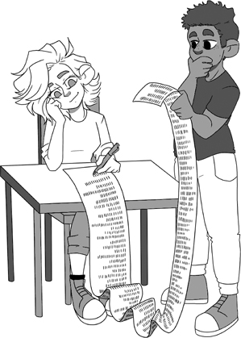

列表是函数式程序中最常见的数据结构。因此，本部分第一章专门讨论列表程序，十分合适。Lists are the most common data structure in functional programs. It is therefore appropriate to devote this first chapter in this Part to programs on lists.

第5章学习编写证明时，我们关闭了Dafny的自动归纳。从现在起，将允许Dafny应用自动归纳。它不会完全消除手工编写证明的需要，但会减少工作量。In Chapter 5, where we were learning to write proofs, we turned off Dafny's automatic induction. From now on, we're going to allow Dafny to apply its automatic induction. This will not eliminate the need for manually written proofs, but it will reduce our work.

## 6.0. 列表定义6.0. List Definition

本章始终使用以下列表数据类型定义：Throughout this chapter, I will use the following definition of a list datatype:

**datatype** List<T> = Nil | Cons(head: T, tail: List<T>)

值Nil表示空列表，Cons(x, xs)表示以元素x开头、随后是列表xs各元素的列表。列表类型以类型T为参数，它是列表中每个元素的类型。The value Nil represents the empty list, whereas Cons(x, xs) represents the list that starts with the element x and then continues with the elements of list xs. The list type is parameterized by a type T, which is the type of every element in the list.

下面是四个列表例子。左侧是可能写在纸上的非形式化记法，中间是相应的List类型表达式，右侧是该列表值的一种类型。Here are four examples of lists. To the left is how you might write each list on a piece of paper. In the middle is the corresponding expression of type List, and to the right is a type for the list value.

[output not shown]

对于任意类型T，元素Nil都可以具有类型List<T>。注意，列表中全部元素的类型相同。以下写法不合法：The element Nil can have type List<T> for any type T. Note that all elements in a list have the same type. It is not legal write

Cons(**true**, Cons(3, Nil)) // error: elements must have common type

## 6.1. Length

下面的函数返回列表长度：Here is a function that returns the length of a list:

**function** Length<T>(xs: List<T>): **nat** {

**match** xs

**case** Nil => 0

**case** Cons(_, tail) => 1 + Length(tail)

}

它说明，空列表长度为0，其他列表比其表尾长1。It says that an empty list has length 0 and other lists are 1 longer than their tail.

这里回顾前几章的两点内容。Here are two little reminders from previous chapters.

第一点，Length的结果类型是**nat**，表示自然数，即非负整数。As a first reminder, the result type of Length is **nat**, which denotes the natural numbers, that is, the non-negative integers.

第二点，Length的定义用**match**表达式区分列表的两个变体。另一种定义方式是使用**if**-**then**-**else**表达式：As a second reminder, the definition of Length uses a **match** expression to distinguish the two variants of lists. An alternative definition would use an **if**-**then**-**else** expression:

**if** xs == Nil **then** 0 **else** 1 + Length(xs.tail)

在**match**与**if**等控制结构之间选择，只是偏好问题；但构造器较多时，通常选择**match**。注意，第一个定义中的tail是**match**分支引入的绑定变量，而第二个定义中的tail是解构器名称，它按照List的数据类型声明，给出Cons的第二个分量。The choice between various control structures, like **match** versus **if**, is simply a matter of taste, but **match** is the typical choice when there are many constructors. Note that tail in the first definition is a bound variable introduced as part of the **match** case, whereas tail in the second definition names the destructor that gives us the second component of a Cons, as defined in the datatype declaration for List.

## 习题6.0。Exercise 6.0.

如上所示，用**match**定义Length，再用上面的**if**定义函数Length’（但递归调用Length’，而非Length）。声明并证明一个引理，说明Length和Length’始终返回相同值。Define Length as above with a **match** and define a function Length’ with the **if** above (but with the recursive call to Length’, not Length). Declare and prove a lemma that says that Length and Length’ always return the same value.

构造器Cons通过把元素放在另一个列表前面来构造列表。有时，我们恰好想反过来：把元素放在另一个列表后面来构造列表，这种操作通常命名为Snoc。由于归纳列表从前往后访问，Snoc的计算成本比Cons高。定义如下：The constructor Cons makes a list by putting an element in front of another list. Sometimes, we want just the opposite—to make a list by putting an element after another list, an operation commonly named Snoc. Because inductive lists are accessed from front to back, Snoc is computationally more expensive than Cons. Here is a definition:

**function** Snoc<T>(xs: List<T>, y: T): List<T> {

**match** xs

**case** Nil => Cons(y, Nil)

**case** Cons(x, tail) => Cons(x, Snoc(tail, y))

}

为了更有信心认为函数定义符合意图，检查它具有某些预期性质总是好主意。可以通过陈述并证明引理来检查。例如，预期Snoc(xs, x)比xs长1：To gain more confidence that we have defined a function as intended, it is always a good idea to check that it has some properties we'd expect. We can do that by stating and proving lemmas. For example, we expect Snoc(xs, x) to be a list 1 longer than xs:

**lemma** LengthSnoc<T>(xs: List<T>, x: T)

**ensures** Length(Snoc(xs, x)) == Length(xs) + 1

{

}

## 习题6.1。Exercise 6.1.

关闭自动归纳，为LengthSnoc编写证明。Turn off automatic induction and write a proof for LengthSnoc.

## 6.2. 内在规约与外在规约6.2. Intrinsic versus Extrinsic Specifications

接下来将遇到两种规约编写风格之间的重要区别。We are about to encounter an important distinction between two styles of writing specifications.

定义函数Append，返回两个列表的连接：Let's define a function Append that returns the concatenation of two lists:

**function** Append<T>(xs: List<T>, ys: List<T>): List<T> {

**match** xs

**case** Nil => ys

**case** Cons(x, tail) => Cons(x, Append(tail, ys))

}

Append与Length之间存在一种关系。用引理刻画它，该引理可自动证明：There is a relation between Append and Length. Let's capture that relation in a lemma, which is proved automatically:

**lemma** LengthAppend<T>(xs: List<T>, ys: List<T>)

**ensures** Length(Append(xs, ys)) == Length(xs) + Length(ys)

{

}

如前所见，引入这样的引理，是陈述并证明函数性质的常用方式。引理陈述的性质称为相对于Append函数定义*外在的*，因为引理不是函数声明本身的一部分。但这并非陈述和证明函数性质的唯一方式。另一种方式，是像方法一样，为函数定义后置条件。函数后置条件给出的性质称为*内在的*，因为它是函数声明的一部分，并在检查函数良构性时一并验证。As we have seen before, introducing a lemma like this is commonly how we state and prove properties of functions. The property stated by the lemma is said to be *extrinsic* to the function definition of Append, because the lemma is not part of the function declaration itself. This is not the only way to state and prove properties of functions. Another way is to define the function with a postcondition, like we do for methods. A property given in a function postcondition is called *intrinsic*, because it is part of the function declaration and is verified as part of checking the well-formedness of the function.

下面是Append的另一种定义，它在内部陈述了引理LengthAppend在外部陈述的性质：Here is an alternative definition of Append that intrinsically states the property that lemma LengthAppend states extrinsically:

**function** Append<T>(xs: List<T>, ys: List<T>): List<T>

**ensures** Length(Append(xs, ys)) == Length(xs) + Length(ys)

{

**match** xs

**case** Nil => ys

**case** Cons(x, tail) => Cons(x, Append(tail, ys))

}

为了引用函数返回的值，后置条件只需提及以该函数参数调用函数的表达式，即Append(xs, ys)。To refer to the value returned by the function, the postcondition simply mentions the function invoked on its parameters, namely Append(xs, ys).

Dafny中的方法始终不透明，因此已知的方法性质，只有方法规约陈述的那些。换句话说，方法的性质始终是内在的，从不是外在的。另一方面，函数透明，因此可以选择以内在或外在方式陈述其性质。Methods in Dafny are always opaque, so the only properties that are known about them are those stated in the method's specification. In other words, properties about methods are always intrinsic, never extrinsic. Functions, on the other hand, are transparent, so we have the choice of stating properties about them intrinsically or extrinsically.

内在规约的一个优点，是每次应用函数时都会使用它。相比之下，验证过程中必须显式应用外在引理，才能使用它陈述的性质。自动使用规约似乎总是优点，但事实并非如此。验证条件变大时，信息过多可能使验证器不堪重负，导致验证耗时很长，甚至验证失败（因为达到了验证器内部某种资源上限）。因此，对函数而言，通常的做法是在外部陈述并证明性质。One advantage of intrinsic specifications is that they get used with every application of the function. In contrast, an extrinsic lemma needs to be applied explicitly in order to make use of its property during verification. Having specifications get used automatically might seem like it would always be an advantage, but it is not. When verification conditions get large, having too much information around may overwhelm the verifier, resulting in long verification times or even in failed verifications (because of reaching some internal resource bounds in the verifier). Therefore, common practice for functions is to state and prove properties extrinsically.

有些情况下，根本无法以内在方式书写性质。当性质多次提及该函数时，就会出现这种情况。例如，无法在函数Mirror的后置条件中陈述性质Mirror(Mirror(t)) == t（第5.7节）。原因是，外层Mirror调用属于递归调用，因此必须证明其实参Mirror(t)小于t。这不可能对所有t都成立：考虑某对具体的t和t’，使t’ == Mirror(t)，这意味着t == Mirror(t’)。显然不能既论证t小于t’，又论证t’小于t。不适合内在规约的其他性质例子，包括交换性和传递性。In some cases, writing a property intrinsically is not even an option. This occurs when the property mentions the function several times. For example, it would not be possible to state the property Mirror(Mirror(t)) == t in the postcondition of function Mirror (Section 5.7). The reason is that the outer call to Mirror is a recursive call, so one would have to prove that its argument, namely Mirror(t), is smaller than t. This is not possible for all t: Consider some particular t and t’ where t’ == Mirror(t), which means that t == Mirror(t’). We certainly cannot argue both that t is smaller than t’ and that t’ is smaller than t. Other examples of properties ill-suited for intrinsic specifications are commutativity and transitivity.

当某性质很可能是函数所有客户都关心的内容时，内在规约才合理且值得推荐。本章把Append的长度视为这一类性质会很方便，因此假定Append定义带有后置条件The one situation where intrinsic specifications make sense and can be recommended occurs when the property is likely to be of concern for all clients of the function. It will be convenient in this chapter to think of the length of Append as falling in that category, so I will assume the definition of Append with the postcondition

Length(Append(xs, ys)) == Length(xs) + Length(ys)

## 习题6.2。Exercise 6.2.

证明Snoc只是Append的特例，即Prove that Snoc is just a special case of Append, that is, that

Snoc(xs, y) == Append(xs, Cons(y, Nil))

### 6.2.0. Append的其他性质6.2.0. Other properties of Append

了解所定义函数的各种代数性质，往往很有用。例如，考虑二元函数⊕，这里把它写成中缀运算符。如果对所有*x*，都有*L* ⊕ *x* = *x*，则值*L*称为⊕的*左单位元*；如果对所有*x*，都有*x* ⊕ *R* = *x*，则值*R*称为⊕的*右单位元*。It is often useful to know various algebraic properties about functions we define. For example, consider a binary function ⊕, which here I will write as an infix operator. A value *L* is called a *left unit element* of ⊕ if, for all *x*, *L* ⊕ *x* = *x*, and a value *R* is called a *right unit element* of ⊕ if, for all *x*, *x* ⊕ *R* = *x*.

根据Append的定义，立即看出Nil是左单位元，即Append(Nil, x) == x。还可以证明Nil是Append的右单位元：By the definition of Append, we see immediately that Nil is a left unit, that is, Append(Nil, x) == x. We can also prove that Nil is a right unit element of Append:

**lemma** AppendNil<T>(xs: List<T>)

**ensures** Append(xs, Nil) == xs

{

}

函数⊕的另一项有用代数性质是*结合性*，表示括号如何分组不影响结果。对于任意*x*、*y*和*z*，Another useful algebraic property of a function ⊕ is *associativity*. It says that it doesn't matter how you parenthesize it. For any *x*, *y*, and *z*,

(*x* ⊕ *y*) ⊕ *z* = *x* ⊕ (*y* ⊕ *z*)

函数Append满足结合律：Function Append is associative:

**lemma** AppendAssociative<T>(xs: List<T>, ys: List<T>, zs: List<T>)

**ensures** Append(Append(xs, ys), zs) == Append(xs, Append(ys, zs))

{

}

## 习题6.3。Exercise 6.3.

给AppendNil添加属性{:induction **false**}，并手工证明该引理。Mark AppendNil with the attribute {:induction **false**} and give a manual proof of the lemma.

## 习题6.4。Exercise 6.4.

给AppendAssociative添加属性{:induction **false**}，并手工证明该引理。Mark AppendAssociative with the attribute {:induction **false**} and give a manual proof of the lemma.

## 习题6.5。Exercise 6.5.

上面看到了Append与Length的一种联系，并选择以内在方式规定它。下面是这两个函数的另一个性质，最好在外部给出。We saw one connection between Append and Length above, and we chose to specify it intrinsically. Here's another property of those two functions, which is best given extrinsically.

**lemma** AppendDecomposition<T>(a: List<T>, b: List<T>,

c: List<T>, d: List<T>)

**requires** Length(a) == Length(c)

**requires** Append(a, b) == Append(c, d)

**ensures** a == c && b == d

分别使用和不使用自动归纳，证明这个引理。Prove this lemma, with and without automatic induction.

## 习题6.6。Exercise 6.6.

对于整数上的运算符，若有左单位元L和右单位元R，证明L与R相等。可以在Dafny中作如下设置：For an operator on the integers with a left unit L and a right unit R, prove that L and R are equal. We can set this up in Dafny as follows:

**function** F(x: **int**, y: **int**): **int**

**const** L: **int**

**const** R: **int**

**lemma** LeftUnit(x: **int**)

**ensures** F(L, x) == x

**lemma** RightUnit(x: **int**)

**ensures** F(x, R) == x

这里，无主体函数F(x, y)表示任意运算（上面写成*x* ⊕ *y*）。名称L和R被声明为任意常量；也可以将它们声明为无主体的零元函数。两个引理陈述F、L和R的性质，以公理形式给出，因此可以直接使用，不要试图证明。陈述并证明一个引理，说明L == R。Here, the body-less function F(x, y) denotes an arbitrary operation (which I had written as *x* ⊕ *y* above). I declared the names L and R as arbitrary constants; an alternative would be to declare them as body-less nullary functions. The two lemmas, which state properties about F, L, and R, are given as axioms, so go ahead and use them but don't try to prove them. State and prove a lemma that L == R.

## 习题6.7。Exercise 6.7.

若对所有*x*，都有*L* ⊕ *x* = *L*，则值*L*称为运算符⊕的*左零元*；若对所有*x*，都有*x* ⊕ *R* = *R*，则值*R*称为⊕的*右零元*。如果运算符有左零元*L*和右零元*R*，这两个元素就相等。针对整数上的任意运算符，陈述并证明此性质。提示：设置方式参见习题6.6。A value *L* is called a *left zero element* of an operator ⊕ if, for all *x*, *L* ⊕ *x* = *L*, and a value *R* is called a *right zero element* of ⊕ if, for all *x*, *x* ⊕ *R* = *R*. If an operator has a left zero element *L* and a right zero element *R*, then these two elements are equal. State and prove this property for an arbitrary operator on the integers. Hint: See Exercise 6.6 for how to set this up.

## 6.3. Take与Drop6.3. Take and Drop

函数Append把两个列表合成一个。函数Take和Drop做相反的事情，把列表分成两部分。Function Append makes two lists into one. The functions Take and Drop do the reverse, they break a list into two parts.

**function** Take<T>(xs: List<T>, n: **nat**): List<T>

**requires** n <= Length(xs)

{

**if** n == 0 **then** Nil **else** Cons(xs.head, Take(xs.tail, n - 1))

}

**function** Drop<T>(xs: List<T>, n: **nat**): List<T>

**requires** n <= Length(xs)

{

**if** n == 0 **then** xs **else** Drop(xs.tail, n - 1)

}

如此带前置条件n <= Length(xs)定义时，这些函数对可以取出或丢弃的元素数量相当挑剔。前置条件使函数体能够在n != 0分支中访问xs.head和xs.tail（这需要xs.Cons?）。Defined with the precondition n <= Length(xs) like this, these functions are rather picky about how many elements can be taken or dropped. The precondition allows the function bodies to access xs.head and xs.tail (which requires xs.Cons?) in the branch where n != 0.

## 习题6.8。Exercise 6.8.

编写无前置条件的、更宽松的Take和Drop版本。如果要求取出的元素多于列表长度，宽松版本返回整个列表；如果要求丢弃的元素多于列表长度，宽松版本返回空列表。证明：如果n <= Length(xs)，宽松版本与上面相应的严格版本返回相同值。Write more liberal versions of Take and Drop that do not have any precondition. Asked to take more elements than the length of the list, the liberal version returns the entire list. Asked to drop more elements than the length of the list, the liberal version return the empty list. Prove that if n <= Length(xs), then the liberal versions return the same value as the respective strict versions above.

## 习题6.9。Exercise 6.9.

关闭自动归纳，证明习题6.8中的引理。With automatic induction turned off, prove the lemma in Exercise 6.8.

很容易证明Append、Take和Drop之间的对应关系：It is easy to prove the correspondence between Append, Take, and Drop:

**lemma** AppendTakeDrop<T>(xs: List<T>, n: **nat**)

**requires** n <= Length(xs)

**ensures** Append(Take(xs, n), Drop(xs, n)) == xs

{

}

**lemma** TakeDropAppend<T>(xs: List<T>, ys: List<T>)

**ensures** Take(Append(xs, ys), Length(xs)) == xs

**ensures** Drop(Append(xs, ys), Length(xs)) == ys

{

}

引理TakeDropAppend的证明利用了函数Append后置条件给出的内在性质。The proof of lemma TakeDropAppend makes use of the intrinsic property given by the postcondition of function Append.

## 习题6.10。Exercise 6.10.

禁用自动归纳，证明引理AppendTakeDrop。Disable automatic induction and prove lemma AppendTakeDrop.

## 习题6.11。Exercise 6.11.

禁用自动归纳，证明引理TakeDropAppend。Disable automatic induction and prove lemma TakeDropAppend.

## 6.4. At

列表的元素有顺序，可以查询给定索引处的元素。The elements of a list are ordered. We can ask for an element at a given index into the list.

**function** At<T>(xs: List<T>, i: **nat**): T

**requires** i < Length(xs)

{

**if** i == 0 **then** xs.head **else** At(xs.tail, i - 1)

}

At的前置条件要求i是列表xs的合法索引。注意，这蕴含xs.Cons?，因而使函数体中使用解构器xs.head和xs.tail合理。The precondition of At requires i to be a proper index into the list xs. Note that this implies xs.Cons?, which justifies our use of the destructors xs.head and xs.tail in the body.

列表xs中位置i的元素，就是前面有i个元素的那个元素。因此，从xs丢弃i个元素后，所获列表的表头就是该元素。尝试把这个性质表述为引理：The element at position i in a list xs is the element preceded by i elements. So, this element is the head of the list you obtain by dropping i elements from xs. Let's try to formulate this property as a lemma:

**lemma** AtDropHead<T>(xs: List<T>, i: **nat**)

**requires** i < Length(xs)

**ensures** At(xs, i) == Drop(xs, i).head // error: .head

// requires Cons?

显然需要为引理设置前置条件，因为要谈论At(xs, i)，必须有i < Length(xs)。但这样陈述引理时，会得到可能访问了没有head的列表的head成员的异议。为了使Drop(xs, i).head定义良好，需要知道Drop(xs, i)返回Cons变体的列表（即非Nil列表）。有几种解决办法。最简单且适合这里的方式，是把Drop(xs, i).Cons?也纳入引理证明目标。于是得到It's clear we need a precondition for the lemma, because to talk about At(xs, i), we must have i < Length(xs). But trying to state the lemma as I did here produces a complaint that we might be access the head member of a list that does not have a head. In order for Drop(xs, i).head to be well-defined, we need to know that Drop(xs, i) returns a list of the Cons variant (that is, a non-Nil list). There are several ways out of this situation. The simplest, which is appropriate here, is to also include Drop(xs, i).Cons? as a proof goal of the lemma. This gives us

**lemma** AtDropHead<T>(xs: List<T>, i: **nat**)

**requires** i < Length(xs)

**ensures** Drop(xs, i).Cons? && At(xs, i) == Drop(xs, i).head

{

}

这可由Dafny自动归纳处理。which is handled by Dafny's automatic induction.

还可以用引理联系At和Append：We also connect At and Append in a lemma:

**lemma** AtAppend<T>(xs: List<T>, ys: List<T>, i: **nat**)

**requires** i < Length(Append(xs, ys))

**ensures** At(Append(xs, ys), i)

== **if** i < Length(xs) **then**

At(xs, i)

**else**

At(ys, i - Length(xs))

{

}

## 边栏6.0Sidebar 6.0

讨论在“旅程”中已走多少步时，数字的含义很清楚。例如，测脉搏时，开始一个6秒的时间段，数“零、一、二、……”When we're talking about how many steps we have taken on a “journey”, it's clear what the numbers mean. For example, when you take your pulse, you start a 6-second interval and count “zero, one, two, . . . ”

再将最后数到的数乘以10，得到每分钟心跳次数。and then you multiply the final number you said by 10 to get your beats per minute.

但如果想给步子本身（这里是每次心跳）命名呢？对此，世界上存在不止一种约定。But what if we want to name the steps (or, in this case, heartbeats) themselves? For that, the world has more than one convention.

如果已经生活了19年，有人问年龄，你会说“19”。出生后的一年中，你正在度过自己的“第0年”。When you have lived for 19 years and someone asks your age, you say “19”. During the year following your birth, you're living your “year 0”.

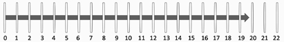

如果公寓位于底层（街道层）往上2层，那么在某些国家（如欧洲大部分地区），要到所在楼层，电梯中按2；而在其他国家（如美国），则按3。If you live in an apartment 2 floors above the ground floor (street level), then in some countries (e.g., most of Europe), you'd press 2 in the elevator to get to your floor, whereas in other countries (e.g., the US), you'd press 3.

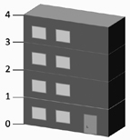

在这里以及其他地方，列表、序列或数组元素的编号从0开始，就像心跳、年龄，以及某些国家的楼层编号。因此，函数At(xs, i)具有前置条件0 <= i < Length(xs)。Here and elsewhere, the names given to elements of a list, sequence, or array start with 0, like heartbeats, ages, and floors in certain countries. Function At(xs, i) therefore has the precondition 0 <= i < Length(xs).

## 习题6.12。Exercise 6.12.

关闭自动归纳，为AtAppend编写证明。提示：采用以下形式的证明：Turn off automatic induction and write a proof for AtAppend. Hint: Use a proof of the form

**match** xs

**case** Nil =>

**case** Cons(x, tail) =>

**if** i == 0 {

// calc…

} **else** {

// calc…

}

（你是不是很庆幸有自动归纳？）(Are you happy about automatic induction?)

## 6.5. Find

定义函数Find，返回元素在列表中的位置。如果元素出现多次，返回第一次出现的索引；如果元素未出现，返回列表长度。换一种更简洁的说法，Find(xs, x)返回xs中不含x的最长前缀的长度。We define a function Find that returns the position of an element in a list. If the element occurs more than once, the index to the first element is returned. If the element does not occur in the list, the length of the list is returned. Stated differently and more concisely, Find(xs, x) returns the length of the longest prefix of xs that does not contain x.

**function** Find<T(==)>(xs: List<T>, y: T): **nat**

**ensures** Find(xs, y) <= Length(xs)

{

**match** xs

**case** Nil => 0

**case** Cons(x, tail) =>

**if** x == y **then** 0 **else** 1 + Find(tail, y)

}

前面的操作完全以元素类型为参数，但函数Find只有在元素类型的值可以比较，即该类型定义了相等关系时才有意义。在Dafny中，每种类型在幽灵上下文中都有相等运算，因此可以把Find写成幽灵函数。但并非每种类型都在编译上下文中提供相等比较。例如，编译代码不能比较两个函数是否相等，因为求值可能需要无限时间。因此，如果想让Find成为编译函数，就必须将类型参数限制为支持编译版相等运算的类型。做法是在类型参数后添加后缀(==)，如上所示（第9.4节会进一步说明）。Whereas our previous operations have been entirely parametric in the element type, function Find only makes sense if the element type is one whose values can be compared, that is, a type on which equality is defined. In Dafny, every type has an equality operation in ghost contexts, so we can write Find as a ghost function. But not every type offers an equality comparison in compiled contexts. For example, you cannot compare two functions for equality in compiled code, for that may take infinite time to evaluate. If we want Find to be a compiled function, we must therefore restrict it to type parameters that support a compiled version of equality. This is done by decorating the type parameter with the suﬃx (==), as I did above (and I'll say more about it in Section 9.4).

## 习题6.13。Exercise 6.13.

删除Find类型参数的后缀(==)。会得到什么错误消息？Remove the suﬃx (==) from Find's type parameter. What error message do you get?

Find(xs, x)始终返回0直至Length(xs)之间的值，两端都包括，这是Find的大多数客户都需要的性质。因此，以内在方式声明此性质：用结果类型**nat**给出下界，用声明的**ensures**子句给出上界。Find(xs, x) always returns a value between 0 and Length(xs), inclusive, which is a property that most clients of Find are going to need. Therefore, we declare this property intrinsically, the lower bound by using result type **nat** and the upper bound by the declared **ensures** clause.

目前见过的各个列表函数有许多可证明的性质。下面只列四例，其中对某个类型T，xs和ys具有类型List<T>，x具有类型T，i具有类型**nat**：Many properties can be proved about the various list functions we have seen so far. Here are but four examples, where xs and ys have type List<T> for some type T, x has type T, and i has type **nat**:

**lemma** AtFind<T>(xs: List<T>, y: T)

**ensures** Find(xs, y) == Length(xs) || At(xs, Find(xs, y)) == y

**lemma** BeforeFind<T>(xs: List<T>, y: T, i: **nat**)

**ensures** i < Find(xs, y) ==> At(xs, i) != y

**lemma** FindAppend<T>(xs: List<T>, ys: List<T>, y: T)

**ensures** Find(xs, y) == Length(xs)

|| Find(Append(xs, ys), y) == Find(xs, y)

**lemma** FindDrop<T>(xs: List<T>, y: T, i: **nat**)

**ensures** i <= Find(xs, y) ==> Find(xs, y) == Find(Drop(xs, i), y) + i

## 习题6.14。Exercise 6.14.

引理AtFind和BeforeFind的证明目标调用了带前置条件的函数At。逐一解释这些调用如何满足前置条件。The proof goals of lemmas AtFind and BeforeFind call function At, which has a precondition. Explain for each of those calls how the precondition is met.

## 习题6.15。Exercise 6.15.

分别使用和不使用自动归纳，证明引理AtFind。Prove lemma AtFind, with and without automatic induction.

## 习题6.16。Exercise 6.16.

分别使用和不使用自动归纳，证明引理BeforeFind。Prove lemma BeforeFind, with and without automatic induction.

## 习题6.17。Exercise 6.17.

分别使用和不使用自动归纳，证明引理FindAppend。Prove lemma FindAppend, with and without automatic induction.

## 习题6.18。Exercise 6.18.

分别使用和不使用自动归纳，证明引理FindDrop。Prove lemma FindDrop, with and without automatic induction.

## 6.6. 列表反转6.6. List Reversal

最后一种列表操作，考虑反转列表元素。下面是一个反转列表的函数：As a final list operation, we consider reversing the elements of a list. Here is one function that reverses a list:

**function** SlowReverse<T>(xs: List<T>): List<T> {

**match** xs

**case** Nil => Nil

**case** Cons(x, tail) => Snoc(SlowReverse(tail), x)

}

这个版本或许容易理解，但执行很慢。更确切地说，SlowReverse(xs)需要的步骤数与xs长度的平方成正比。我们将编写更高效的版本，并证明它输出的值与这个慢版本相同。但首先，至少证明SlowReverse(xs)与xs长度相同。This version may be easy to understand, but it would execute slowly. To be more precise, SlowReverse(xs) requires a number of steps proportional to the square of the length of xs. We will write a more eﬃcient version and prove that it outputs the same value as this slow version. But first, let us at least prove that SlowReverse(xs) has the same length as xs.

**lemma** LengthSlowReverse<T>(xs: List<T>)

**ensures** Length(SlowReverse(xs)) == Length(xs)

试着预测证明需要什么。查看SlowReverse定义，预期Nil分支立即满足引理。对于Cons分支，归纳假设给出SlowReverse(tail)与tail长度相同，因此只要有Snoc使列表长度增加1的事实，就能完成。试试看：Let's see if we can predict what is needed for its proof. Looking at the definition of SlowReverse, we expect the Nil case to immediately satisfy the lemma. In the Cons case, the induction hypothesis will give us that SlowReverse(tail) has the same length as tail, so if we only have the fact that Snoc increases the list length by 1, then we would be done. Let's try that:

{

**match** xs

**case** Nil =>

**case** Cons(x, tail) =>

LengthSnoc(SlowReverse(tail), x);

}

确实，验证器能补上其余细节。Indeed, the verifier is able to fill in the rest of the details.

编写更高效列表反转版本的技巧，是添加所谓*累加器*参数，记录目前已反转的部分。更确切地说，辅助函数ReverseAux(xs, acc)的设想是返回Append(xs’, acc)，其中xs’是列表xs反转后的结果。定义如下：The trick to writing a more eﬃcient version of list reversal is to add what is called an *accumulator* parameter that keeps track of the part that has been reversed so far. More precisely, the idea for our auxiliary function ReverseAux(xs, acc) is that it return Append(xs’, acc), where xs’ is the list xs reversed. Here is the definition:

**function** ReverseAux<T>(xs: List<T>, acc: List<T>): List<T>

{

**match** xs

**case** Nil => acc

**case** Cons(x, tail) => ReverseAux(tail, Cons(x, acc))

}

要反转Cons(x, tail)并在后面接上acc，就反转tail，再在其后接上Cons(x, acc)。To reverse Cons(x, tail) and append acc to it, we reverse tail and append Cons(x, acc) to it.

如果编写的是方法，大概会在**ensures**子句中记录ReverseAux的预期效果，作为内在规约。对于ReverseAux也可以这样做。首先，预期辅助函数只有一个其他调用者，因此适用内在规约的指导原则：每个调用者都关心这个性质。不过，验证该性质需要提供一些手工指引。第6.7节将展示如何做。现在，先在外部陈述并证明这个性质。If we were writing a method, we would probably have recorded the intended effect of ReverseAux in an **ensures** clause, as an intrinsic specification. We could do that for ReverseAux. For one, we expect only one other caller of the auxiliary function, so our guiding principle of using an intrinsic specification applies: every caller is interested in this property. However, to verify the property, we need to provide some manual guidance. I will show how to do that in Section 6.7. For now, let's state and prove the property extrinsically.

**lemma** ReverseAuxSlowCorrect<T>(xs: List<T>, acc: List<T>)

**ensures** ReverseAux(xs, acc) == Append(SlowReverse(xs), acc)

{

**match** xs

**case** Nil =>

**case** Cons(x, tail) =>

**calc** {

Append(SlowReverse(xs), acc);

== // def. SlowReverse

Append(Snoc(SlowReverse(tail), x), acc);

证明从右侧开始，因为右侧更复杂，可能提供更好的指引。应用SlowReverse的定义后，或许希望应用Snoc定义。由于不知道Snoc的两个分支中适用哪一个，就得把Snoc的整个定义带入演算。有时必须这样做。不过，在当前情形中，也可以改用Append来改写Snoc。In the proof, we start with the right-hand side, since it is more complicated and may therefore give us better guidance. After applying the definition of SlowReverse, we may hope to apply the definition of Snoc. Since we are not in a situation where we know which of the two cases of Snoc applies, we would need to bring in the entire definition of Snoc into the calculation. Sometimes, this is what we have to do. In the current situation, however, we have the alternative of rewriting Snoc in terms of Append.

== { SnocAppend(SlowReverse(tail), x); }

Append(Append(SlowReverse(tail), Cons(x, Nil)), acc);

这里可以应用Append的结合律。Here, we can apply the associativity of Append.

== { AppendAssociative(SlowReverse(tail), Cons(x, Nil), acc); }

Append(SlowReverse(tail), Append(Cons(x, Nil), acc));

将acc接在单元素列表Cons(x, Nil)之后，得到以x开头、以acc结尾的列表。我们没有为这一性质命名的引理，但它可由Append定义展开两次得出。为记录这一证明步骤，在提示中使用断言。Appending acc to the singleton list Cons(x, Nil) will give a list that starts with x and ends with acc. We don't have a named lemma for this property, but it follows from two unrollings of the definition of Append. To document this proof step, we use an assertion in the hint.

== { **assert** Append(Cons(x, Nil), acc) == Cons(x, acc); }

Append(SlowReverse(tail), Cons(x, acc));

现在公式的形状与正在证明的引理相似，因此应用归纳假设。The formula now has a shape like that in the lemma we are trying to prove, so we invoke the induction hypothesis.

== { ReverseAuxSlowCorrect(tail, Cons(x, acc)); }

ReverseAux(tail, Cons(x, acc));

验证器现在接受证明了。事实上，在显式应用归纳假设之前它就已接受，因为自动归纳已经处理了这一点。但为了完成一个可读的证明，再做一步：The verifier is now happy with the proof. Actually, the verifier was happy even before our explicit invocation of the induction hypothesis, because that was taken care of by automatic induction. But to finish up a readable proof, we take one more step:

== // def. ReverseAux

ReverseAux(xs, acc);

}

}

现在已证明ReverseAux符合意图。剩下的工作是，在函数Reverse中使用它，并证明最终结果与应用SlowReverse相同。We have now proved that ReverseAux does what we intended. What remains is to use it in a function Reverse and to prove that the end result is the same as applying SlowReverse.

**function** Reverse<T>(xs: List<T>): List<T> {

ReverseAux(xs, Nil)

}

正确性证明利用了Nil是Append右单位元这一事实，除此之外很直接。The proof of correctness makes use of the fact that Nil is a right unit element of Append, but is otherwise straightforward.

**lemma** ReverseCorrect<T>(xs: List<T>)

**ensures** Reverse(xs) == SlowReverse(xs)

{

**calc** {

Reverse(xs);

== // def. Reverse

ReverseAux(xs, Nil);

== { ReverseAuxSlowCorrect(xs, Nil); }

Append(SlowReverse(xs), Nil);

== { AppendNil(SlowReverse(xs)); }

SlowReverse(xs);

}

}

由于Reverse比SlowReverse高效，编译代码中更愿意使用前者。为了在源代码中体现这一点，可以把SlowReverse声明为幽灵函数。Since Reverse is more eﬃcient than SlowReverse, we prefer it for compiled code. To make note of this in the source code, you can declare SlowReverse to be a ghost function.

Reverse和SlowReverse除执行时间外相同，这意味着它们具有相同性质。例如，现在可以用Reverse而非SlowReverse陈述ReverseAux的正确性引理。The fact that Reverse and SlowReverse are the same, except for their execution time, means that they have the same properties. For example, we can now state the correctness lemma about ReverseAux in terms of Reverse instead of SlowReverse.

**lemma** ReverseAuxCorrect<T>(xs: List<T>, acc: List<T>)

**ensures** ReverseAux(xs, acc) == Append(Reverse(xs), acc)

{

ReverseCorrect(xs);

ReverseAuxSlowCorrect(xs, acc);

}

类似地，由Reverse与SlowReverse之间的联系，以及已证明SlowReverse保持长度的引理，可以得出列表反转不改变长度。Similarly, the fact that the reversal of a list does not change its length follows from the connection between Reverse and SlowReverse and the lemma we already proved about SlowReverse preserving length.

**lemma** LengthReverse<T>(xs: List<T>)

**ensures** Length(Reverse(xs)) == Length(xs)

{

ReverseCorrect(xs);

LengthSlowReverse(xs);

}

## 习题6.19。Exercise 6.19.

对于任意列表xs和acc，证明Length(ReverseAux(xs, acc)) == Length(xs) + Length(acc)。Prove Length(ReverseAux(xs, acc)) == Length(xs) + Length(acc), for any lists xs and acc.

## 习题6.20。Exercise 6.20.

利用习题6.19的引理，为LengthReverse编写另一种证明。Write an alternative proof for LengthReverse that uses the lemma in Exercise 6.19.

一个值得考虑的有趣性质，是两个列表连接后的反转。先从联系ReverseAux与Append的性质开始。An interesting property to consider is the reversal of the concatenation of two lists. We start with a property that relates ReverseAux and Append.

**lemma** ReverseAuxAppend<T>(xs: List<T>, ys: List<T>, acc: List<T>)

**ensures** ReverseAux(Append(xs, ys), acc)

== Append(Reverse(ys), ReverseAux(xs, acc))

{

**match** xs

**case** Nil =>

ReverseAuxCorrect(ys, acc);

**case** Cons(x, tail) =>

}

不同寻常的是，这个证明在Nil分支需要手工步骤，而在Cons分支会自动通过。Unusually, this proof requires a manual step in the Nil case and goes through automatically in the Cons case.

## 习题6.21。Exercise 6.21.

给引理ReverseAuxAppend添加{:induction **false**}，并为Cons分支编写演算式证明。Mark lemma ReverseAuxAppend with {:induction **false**} and write a calculational proof for the Cons case.

## 习题6.22。Exercise 6.22.

证明以下引理：Prove the following lemma:

**lemma** ReverseAppend<T>(xs: List<T>, ys: List<T>)

**ensures** Reverse(Append(xs, ys))

== Append(Reverse(ys), Reverse(xs))

## 习题6.23。Exercise 6.23.

证明Reverse是对合。也就是说，证明Prove that Reverse is an involution. That is, prove that

Reverse(Reverse(xs)) == xs

提示：使用本节前面的引理以及习题6.22中的引理。Hint: Use lemmas from earlier in this section and from Exercise 6.22.

## 6.7. 表达式中的引理6.7. Lemmas in Expressions

我们使用了三种证明编写构造：内联断言、证明演算和引理调用。它们都是语句，我们在方法体和引理主体中用它们帮助完成证明义务。确立函数良构性也有证明义务。目前所有这类函数证明义务都自动通过了，但许多函数并非如此。We have used three proof-authoring constructs: inline assertions, proof calculations, and lemma calls. These are statements, and we used them in method bodies and lemma bodies to help discharge proof obligations. There are also proof obligations to establish the well-formedness of functions. So far, all such proof obligations for functions have gone through automatically, but there are plenty of functions where this is not the case.

虽然Dafny表达式中不能使用一般语句，但可以使用证明编写语句。如果S是内联断言、证明演算或引理调用，E是表达式，那么S E也是表达式。例如，**assert** 0 < x; 100 / x是表达式。Although general statements cannot be used in expressions in Dafny, proof-authoring statements can be. If S is an inline assertion, proof calculation, or lemma call, and E is an expression, then S E is also an expression. For example, **assert** 0 < x; 100 / x is an expression.

表达式S E的值就是E。语句S不影响E的值。事实上，S部分始终是幽灵构造，编译时被擦除，运行时不存在。证明编写语句S只用于帮助确立E中产生的证明义务（以及外围表达式中E之后的证明义务）。例如，**assert** 0 < x; 100 / x的值为100 / x，但除数x非零的证明义务由断言**assert** 0 < x;推出。当然，S部分本身也可能产生证明义务（例如语句为**assert** 0 < x时的0 < x），这些也必须确立。The value of an expression S E is simply E. The statement S does not affect the value of E. In fact, the S part is always ghost, so it is erased during compilation and is not present at run time. The proof-authoring statement S is used only to help establish any proof obligations that arise in E (and downstream of E in any enclosing expression). For example, the value of **assert** 0 < x; 100 / x is 100 / x, but the proof obligation that the divisor x is non-zero follows from the assertion **assert** 0 < x;. Of course, the S part may itself entail proof obligations (like 0 < x when the statement is **assert** 0 < x) and these need to be established as well.

接下来两个例子在表达式中使用证明编写构造。The next two examples make use of proof-authoring constructs in expressions.

### 6.7.0. ReverseAux的内在规约6.7.0. Intrinsic specification of ReverseAux

在第6.6节，证明了ReverseAux正确实现意图的引理。我曾论述，这个性质很适合以内在方式陈述，即作为函数的**ensures**子句。为此，将ReverseAux声明如下：In Section 6.6, we proved a lemma that ReverseAux correctly implements our intent. I argued that this property is a good candidate to be stated intrinsically, that is, as an **ensures** clause of the function. To do that, we declare ReverseAux as follows:

**function** ReverseAux<T>(xs: List<T>, acc: List<T>): List<T>

**ensures** ReverseAux(xs, acc) == Append(SlowReverse(xs), acc)

{

**match** xs

**case** Nil => acc

**case** Cons(x, tail) =>

ReverseAux(tail, Cons(x, acc)) // error: cannot prove postcondition

}

遗憾的是，验证器无法从给定函数体自动证明后置条件。更确切地说，验证器无法证明：**ensures**子句中表示本次函数调用结果值的ReverseAux(xs, acc)等于Alas, the verifier is unable to prove this postcondition automatically from the given function body. More precisely, the verifier is unable to show that ReverseAux(xs, acc), which in the **ensures** clause denotes the result value of the function invocation, equals

Append(SlowReverse(xs), acc)

为了帮助验证器，在递归调用前插入证明演算，表明该表达式等于To help the verifier along, let us insert a proof calculation before the recursive call, showing that this expression equals

Append(SlowReverse(xs), acc)

**function** ReverseAux<T>(xs: List<T>, acc: List<T>): List<T>

**ensures** ReverseAux(xs, acc) == Append(SlowReverse(xs), acc)

{

**match** xs

**case** Nil => acc

**case** Cons(x, tail) =>

**calc** {

Append(SlowReverse(xs), acc);

== // def. SlowReverse

Append(Snoc(SlowReverse(tail), x), acc);

== { SnocAppend(SlowReverse(tail), x); }

Append(Append(SlowReverse(tail), Cons(x, Nil)), acc);

== { AppendAssociative(SlowReverse(tail), Cons(x, Nil), acc); }

Append(SlowReverse(tail), Append(Cons(x, Nil), acc));

== { **assert** Append(Cons(x, Nil), acc) == Cons(x, acc); }

Append(SlowReverse(tail), Cons(x, acc));

== // postcondition of ReverseAux

ReverseAux(tail, Cons(x, acc));

}

ReverseAux(tail, Cons(x, acc))

}

证明演算本身与第6.6节外在引理ReverseAuxSlowCorrect中的相同，只是不包含先前演算中借助ReverseAux定义的最后一行。The proof calculation itself is identical to the one we wrote in the extrinsic lemma ReverseAuxSlowCorrect in Section 6.6, except that we do not include the last line of the previous calculation that appealed to the definition of ReverseAux.

注意，虽然证明演算用于帮助证明外围函数的后置条件，但它位于ReverseAux最终表达式*之前*。因为语法始终是S E，其中S为证明编写语句，E为表达式。如果更喜欢相反顺序，可以使用let表达式：Note that the proof calculation goes *before* the final expression of ReverseAux, even though we're using it to help prove the postcondition of the enclosing function. This is because the syntax is always S E, where S is a proof-authoring statement and E is an expression. If you prefer to see it in the other order, you can use a let expression:

**var** r := ReverseAux(tail, Cons(x, acc));

**calc** {

// proof calculation goes here

}

r

无论偏好哪种表述，在函数ReverseAux主体中加入证明演算，就能以内在方式给出ReverseAux的正确性性质。缺点是使函数体变杂乱。（再次强调，这不影响函数运行时行为，但使人更难阅读函数。）因此，还有一种办法：把证明演算重构为独立引理，再从ReverseAux函数体中调用它：Regardless of which of these formulations you prefer, having the proof calculation in the body of function ReverseAux allows us to give the ReverseAux correctness property intrinsically. On the downside, it clutters up the body of the function. (Again, this does not affect the run-time behavior of the function, but it makes the function more diﬃcult to read for a human). So, yet another alternative is to refactor the proof calculation into a separate lemma and to call this lemma from the function body of ReverseAux:

**function** ReverseAux<T>(xs: List<T>, acc: List<T>): List<T>

**ensures** ReverseAux(xs, acc) == Append(SlowReverse(xs), acc)

{

**match** xs

**case** Nil => acc

**case** Cons(x, tail) =>

ReverseAuxHelper(xs, acc);

ReverseAux(tail, Cons(x, acc))

}

**lemma** ReverseAuxHelper<T>(xs: List<T>, acc: List<T>)

**requires** xs.Cons?

**ensures** ReverseAux(xs.tail, Cons(xs.head, acc))

== Append(SlowReverse(xs), acc)

**decreases** xs, acc, 0

{

**var** x, tail := xs.head, xs.tail;

**calc** {

Append(SlowReverse(xs), acc);

== // def. SlowReverse

Append(Snoc(SlowReverse(tail), x), acc);

== { SnocAppend(SlowReverse(tail), x); }

Append(Append(SlowReverse(tail), Cons(x, Nil)), acc);

== { AppendAssociative(SlowReverse(tail), Cons(x, Nil), acc); }

Append(SlowReverse(tail), Append(Cons(x, Nil), acc));

== { **assert** Append(Cons(x, Nil), acc) == Cons(x, acc); }

Append(SlowReverse(tail), Cons(x, acc));

== // postcondition of ReverseAux

ReverseAux(tail, Cons(x, acc));

}

}

注意，这一变换使函数ReverseAux与ReverseAuxHelper相互递归：函数调用引理，而引理在其后置条件和主体中使用函数。因此，需要考虑终止性。由于ReverseAux没有显式**decreases**子句，Dafny默认使用字典序元组xs, acc，即函数参数。对于引理本来也会这样做，但这样函数调用引理时就没有任何减小。于是手工为引理编写**decreases**子句。采用以xs, acc开头的任意字典序三元组即可，因为Dafny把较长元组排在较短元组的严格下方（参见第3.3.3节）。Note that this transformation makes the function ReverseAux mutually recursive with ReverseAuxHelper—the function calls the lemma and the lemma uses the function (in both its postcondition and its body). This means that we need to think about termination. Since ReverseAux does not have an explicit **decreases** clause, Dafny by default uses the lexicographic tuple xs, acc (that is, the parameters of the function). It would do the same for the lemma, but then nothing is decreased when the function calls the lemma. Instead, we manually write a **decreases** clause for the lemma. It suﬃces to take any lexicographic triple that starts with xs, acc, since Dafny orders the longer tuple strictly below the shorter one (see Section 3.3.3).

## 习题6.24。Exercise 6.24.

函数ReverseAux和引理ReverseAuxHelper的**decreases**子句中的acc分量从未使用。为ReverseAux和ReverseAuxHelper编写显式**decreases**子句，证明终止性，但不提及acc。The acc component of the **decreases** clauses of function ReverseAux and lemma ReverseAuxHelper is never used. Write explicit **decreases** clauses for ReverseAux and ReverseAuxHelper that prove termination and do not mention acc.

### 6.7.1. 关于At与Reverse的引理6.7.1. Lemma about At and Reverse

再举一个表达式良构性需要证明的例子。考虑一个引理，说明列表xs从开头数、前面有i个元素的那个元素，与Reverse(xs)从末尾数、后面有i个元素的那个元素相同：Here is one more example where the well-formedness of expressions requires a proof. We consider a lemma that states that the first-but-i element of a list xs is the same as the last-but-i element of Reverse(xs):

**lemma** AtReverse<T>(xs: List<T>, i: **nat**)

**requires** i < Length(xs)

**ensures** At(xs, i) == At(Reverse(xs), Length(xs) - 1 - i)

// possible precondition violation on previous line

按当前写法，引理陈述并非定义良好。问题在于At要求合法索引。引理前置条件说明i是xs的合法索引，但如果不知道更多关于Reverse(xs)长度的信息，就不清楚Length(xs) - 1 - i是否为Reverse(xs)的合法索引。可以把这一点作为另一个后置条件：As written, the statement of this lemma is not well-defined. The problem is that At requires a proper index. The precondition of the lemma tells us that i is a proper index into xs, but without knowing more about the length of Reverse(xs), it is not clear that Length(xs) - 1 - i is a proper index into Reverse(xs). We could add this as another postcondition:

**lemma** AtReverse<T>(xs: List<T>, i: **nat**)

**requires** i < Length(xs)

**ensures** Length(xs) - 1 - i < Length(Reverse(xs))

**ensures** At(xs, i) == At(Reverse(xs), Length(xs) - 1 - i)

这类似于在第6.4节中给引理AtDropHead添加额外的后置条件合取项。但这里，额外合取项只会使引理陈述杂乱。另一种做法是，为了让Dafny确信At调用确实满足前置条件，调用引理LengthReverse，而且直接在后置条件表达式中调用！akin to the extra postcondition conjunct we added to lemma AtDropHead in Section 6.4. Here, however, this extra conjunct only clutters up the statement of the lemma. Instead, to convince Dafny that the call to At does satisfy its precondition, we invoke the lemma LengthReverse and we do so in the postcondition expression itself!

**lemma** AtReverse<T>(xs: List<T>, i: **nat**)

**requires** i < Length(xs)

**ensures** (LengthReverse(xs);

At(xs, i) == At(Reverse(xs), Length(xs) - 1 - i))

（为向后兼容以分号结尾的规约子句，Dafny允许在规约子句末尾添加可选分号。这种支持带来的一个不便是：对于像这个后置条件这样调用引理的规约子句，需要在外面加括号。）(For backward compatibility with specification clauses that end with a semi-colon, Dafny allows an optional semi-colon at the end of specification clauses. An unfortunate consequence of this support is that we need to wrap parentheses around a specification clause that calls a lemma, like this postcondition.)

在引理主体中，希望使用从At(Reverse(xs), Length(xs) - 1 - i)开始的证明演算。这再次引发抱怨：可能向At传入非法索引。后置条件中新添的LengthReverse调用给出关于Length(Reverse(xs))的信息，供后置条件其余部分使用，但不会使主体获得这些信息。因此，还需要在主体中调用引理。In the body of this lemma, we would like to use a proof calculation that starts with At(Reverse(xs), Length(xs) - 1 - i). Again, this bites us with a complaint that we may be passing an improper index to At. Our new call to LengthReverse in the postcondition gives information about Length(Reverse(xs)), which is used in the rest of the postcondition, but this does not make the information available in the body. Instead, we need to invoke the lemma in the body as well.

很快还会发现，给xs的表头和表尾命名会很方便，于是引入局部变量保存它们。正如在第6.4节引入函数At时所指出的，前置条件i < Length(xs)蕴含xs.Cons?。因此，AtReverse主体这样开头：Soon, it will also be convenient to have names for the head and tail of xs, so we introduce local variables to hold these. As I remarked with the introduction of function At in Section 6.4, note that the precondition i < Length(xs) implies xs.Cons?. Okay, so we start the body of AtReverse like this:

{

**var** x, tail := xs.head, xs.tail;

LengthReverse(xs);

**calc** {

At(Reverse(xs), Length(xs) - 1 - i);

== // def. Reverse

At(ReverseAux(xs, Nil), Length(xs) - 1 - i);

== // def. ReverseAux

At(ReverseAux(tail, Cons(x, Nil)), Length(xs) - 1 - i);

== { ReverseAuxSlowCorrect(tail, Cons(x, Nil)); }

At(Append(SlowReverse(tail), Cons(x, Nil)), Length(xs) - 1 - i);

== { ReverseCorrect(tail); }

At(Append(Reverse(tail), Cons(x, Nil)), Length(xs) - 1 - i);

这些演算步骤相当直接。讨论了这么多表达式良构性，你可能想知道，为何Dafny不抱怨演算第二行及后续行中的At前置条件。这是因为Dafny检查演算某一行的良构性时，会假定前一行良构。这通常进行得如此顺畅，以至于你可能根本没想到还需要检查。These steps in the calculation are fairly straightforward. With all this talk about the well-formedness of expressions, you may be wondering why Dafny does not complain about the precondition of At in the second and subsequent lines of the calculation. This is because when Dafny checks the well-formedness of a line in a calculation, it assumes the well-formedness of the previous line. This usually works so smoothly that you probably did not even think about that it had to be checked.

证明当前行对Append应用At。引理AtAppend说明，这种表达式可改写为对Append的第一个或第二个列表实参应用At。但在证明的此阶段，无法判断会是哪部分，因此必须保留**if**-**then**-**else**表达式：The current line in our proof performs an At of an Append. The AtAppend lemma tells us that such an expression can be rewritten into an At of either the first or second list argument to Append. However, at this stage in the proof, we cannot tell which part it will be, so we must keep the **if**-**then**-**else** expression:

== { AtAppend(Reverse(tail), Cons(x, Nil), Length(xs) - 1 - i); }

**if** Length(xs) - 1 - i < Length(Reverse(tail)) **then**

At(Reverse(tail), Length(xs) - 1 - i)

**else**

At(Cons(x, Nil), Length(xs) - 1 - i-Length(Reverse(tail)));

不要因表达式长而气馁。相反，简化它的部分，使其更容易理解：Let's not be discouraged by the length of this expression. Instead, let us simplify parts of it to make it easier to understand:

== { LengthReverse(tail); }

**if** Length(xs) - 1 - i < Length(tail) **then**

At(Reverse(tail), Length(xs) - 1 - i)

**else**

At(Cons(x, Nil), Length(xs) - 1 - i - Length(tail));

== // arithmetic, using Length(xs) == Length(tail) + 1 and 0 <= i

**if** 0 < i **then**

At(Reverse(tail), Length(tail) - 1 - (i - 1))

**else**

At(Cons(x, Nil), 0);

现在，如果在演算中继续带着**if**往下走，只会更加杂乱。因此，结束演算，分成两种情况，其中一种由验证器自动证明：Alright, now things would get messier if we just continued carrying the **if** forward in the calculation. Instead, let us close the calculation and break into two cases, one of which is proved automatically by the verifier:

}

**if** 0 < i {

在此条件保护下，希望从At(Reverse(tail), Length(tail) - 1 - (i - 1))这一行继续演算。新演算不会记得其他演算步骤的良构性，因此需要再次调用LengthReverse引理，这次针对tail。Guarded by this condition, we would like to continue our calculation from the line At(Reverse(tail), Length(tail) - 1 - (i - 1)). A new calculation will not remember the well-formedness of steps of some other calculation, so we need to invoke the LengthReverse lemma once more, this time on tail.

LengthReverse(tail);

**calc** {

At(Reverse(tail), Length(tail) - 1 - (i - 1));

好消息是快完成了。这个表达式具有正在证明的引理的形式，因此应用归纳假设，证明就基本大功告成了。Well, the good news is that we are almost done. This expression has the form of the lemma we are trying to prove, so we invoke the induction hypothesis, and that just about wraps ’er up.

== { AtReverse(tail, i - 1); }

At(tail, i - 1);

== // def. At

At(xs, i);

}

}

}

陈述和证明该引理时，多次借助引理LengthReverse。如果把LengthReverse性质写成函数Reverse的后置条件，就能避免这些引理调用。编写这样的内在规约很诱人，有时也确实很好。它们自动向验证器引入更多事实，从而简化证明任务。但如前所述，更复杂的情况下，这些额外事实可能使验证器不堪重负。因此，要节制地使用内在规约。In stating and proving this lemma, we had to make several appeals to lemma LengthReverse. We could have avoided the need for these lemma calls if we had instead written the LengthReverse property as a postcondition of function Reverse. Writing such intrinsic specifications is tempting, and sometimes they are a good idea. They do simplify our proof task by automatically introducing more facts for the verifier. However, as I have mentioned, in more complex situations, these additional facts may just overwhelm the verifier. So, use intrinsic specifications sparingly.

## 习题6.25。Exercise 6.25.

在第6.4节中，最初陈述引理AtDropHead时遇到问题，因为证明目标中的表达式本身并非定义良好。陈述一个引理In Section 6.4, we came across an initial problem with stating lemma AtDropHead, because the expression in the proof goal was not well-defined by itself. State a lemma

**lemma** DropLessThanEverything<T>(xs: List<T>, i: **nat**)

**requires** i < Length(xs)

**ensures** Drop(xs, i).Cons?

并在最初尝试编写的引理AtDropHead的证明目标中使用它。然后证明DropLessThanEverything和新写的AtDropHead。and use this lemma in the proof goal of the original attempt at writing lemma AtDropHead. Then, prove both DropLessThanEverything and your new AtDropHead.

## 6.8. 省略类型实参6.8. Eliding Type Arguments

本节见到了许多关于列表的函数和引理示例。所有示例中，列表元素类型都是抽象的。也就是说，函数和引理以一个类型为参数，本章恰好始终把它命名为T。由于这些载荷的具体类型无关紧要，你可能觉得下列类型签名In this section, we have seen numerous examples of functions and lemmas about lists. In all of these examples, the list element type was abstract. That is, our functions and lemmas were parameterized by a type, which in this chapter I happened to always name T. Since the specific type of this payload is irrelevant, you may have the feeling that type signatures like

**function** ReverseAux<T>(xs: List<T>, acc: List<T>): List<T>

过于冗长或杂乱。当无需单独列出类型T时，Dafny有一条省略规则，让你完全不必提及T。本书其他地方会使用这条省略规则的两种形式。它似乎是Dafny独有的，因此在这里解释这两种形式。are overly verbose or cluttered. When you don't have any need for listing the type T by itself, Dafny has an elision rule that saves you from mentioning T at all. I will use two forms of this elision rule in other parts of the book. The elision rule appears to be unique to Dafny, so I will explain those forms here.

回想一下，在Dafny中，List这样的参数化类型必须用某个类型实参实例化，例如List<**int**>，或List<T>，其中T是类型参数。在函数、方法或引理的类型签名中，如果提到参数化类型而未给出任何类型实参（即没有用于给出类型实参的尖括号），就自动填入外围函数、方法或引理的类型参数列表。这一形式的省略规则意味着，上面的函数ReverseAux类型签名可写为Recall that, in Dafny, a parameterized type like List must always be instantiated with some type argument; for example, List<**int**>, or List<T> where T is type parameter. In the type signature of a function, method, or lemma, any parameterized type that is mentioned without any type arguments (that is, without the angle brackets where such type arguments would be given) gets filled in automatically with the list of type parameters of the enclosing function, method, or lemma. This form of the elision rule means that the type signature of function ReverseAux above can be given as

**function** ReverseAux<T>(xs: List, acc: List): List

此外，函数Length（第6.1节）的类型签名可写为Also, the type signature of function Length (Section 6.1) can be given as

**function** Length<T>(xs: List): **nat**

而函数At（第6.4节）的类型签名可写为and the type signature of function At (Section 6.4) can be given as

**function** At<T>(xs: List, i: **nat**): T

省略规则的另一种形式是：如果函数、方法或引理的类型参数没有在其他任何地方提及，也可以省略它。因此，ReverseAux和Length的类型签名可进一步缩写为The other form of the elision rule is that, if the function, method, or lemma's type parameter is not mentioned anywhere else, then it, too, can be elided. So, the type signatures of ReverseAux and Length can be abbreviated further as

**function** ReverseAux(xs: List, acc: List): List

以及and

**function** Length(xs: List): **nat**

但是，第二条省略规则对函数At没有进一步帮助，因为At需要用该类型参数作为结果类型。However, this second elision rule is of no further help for function At, because At needs to mention the type parameter as its result type.

## 习题6.26。Exercise 6.26.

利用省略规则，缩短Append, Take, AtAppend, Find, AtDropHead以及Reverse的签名。Make use of the elision rules to shorten the signatures of Append, Take, AtAppend, Find, AtDropHead, and Reverse.

## 6.9. 小结6.9. Summary

本章介绍了函数式编程中广泛使用的数据类型List。由于List操作定义为递归函数，陈述其性质的引理很适合用归纳法证明。In this chapter, I introduced the datatype List, which is used throughout functional programming. Since operations on List are defined as recursive functions, lemmas that state properties of the operations are a good match for inductive proofs.

把函数性质声明为函数后置条件，称为*内在*规约。它是函数不可分割的一部分，必须在证明函数良构性的过程中证明。A property of a function that is declared as a postcondition of the function is called an *intrinsic* specification. It is an integral part of the function and has to be proved as part of showing the well-formedness of the function.

把函数性质与函数分开、作为引理声明，称为*外在*规约。它通过查看函数定义来证明，并且很容易陈述涉及多次函数调用的性质，例如结合律。A property of a function that is declared separately from the function, as a lemma, is called an *extrinsic* specification. It is proved by looking at the definition of the function and can easily state properties that involve multiple invocations of the function, such as associativity.

本章还展示了：使用累加器获得更高效的函数实现；使用类型特征(==)，表示类型支持编译的相等运算（第9.4节将进一步讨论）；确保表达式定义良好的各种技巧，包括在表达式中使用证明编写语句；以及Dafny在函数、方法和引理签名中省略类型参数的规则。In the chapter, I also showed the use of an accumulator to obtain a more eﬃcient implementation of a function; the use of the type characteristic (==), which says a type supports compiled equality operations (more about that in Section 9.4); various techniques for making sure expressions are well-defined, including the use of proof-authoring statements in expressions; and Dafny's rule for eliding type parameters in the signatures of functions, methods, and lemmas.

## 注释Notes

在Dafny中，函数或方法后置条件的定义良好性必须由前置条件推出，而不考虑函数或方法主体。SPARK [43]和OpenJML [105]的做法不同：对于带有主体的函数或方法，在退出主体处检查后置条件的定义良好性。In Dafny, the well-definedness of a function or method's postcondition must follow from the precondition, without regard to the body of the function or method. This is done differently in SPARK [43] and OpenJML [105], where for a function or method with a body, the well-definedness of the postcondition is checked on exit from the body.

## 边栏6.1Sidebar 6.1

假设一本书有18章，翻开后，左边有7章，右边有其余11章，如图所示：Suppose you have a book with 18 chapters and you open it so that 7 chapters fall to the left and the other 11 chapters fall to the right, as depicted here:

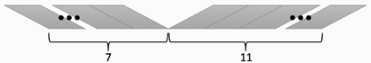

如果已读到翻开的地方，那么已经读了7章。If you have read to the place where you have opened the book, then you have read 7 chapters.

用数字给各章命名。这个展开页中可见的章节该叫什么？显然，用“7”命名左边或右边的章节很方便。但究竟是哪边？Let's use numbers to name the chapters. What shall we name the chapters visible in this spread? Certainly, it will be convenient to use “7” to name either the chapter on the left or the chapter on the right. But which one?

如果在这个展开页中印上“7”，两种选择就归结为写成If we print “7” in this spread, then the two choices come down to writing

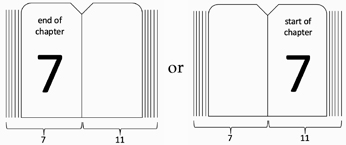

就我而言，我喜欢开始读某章时就看到章名，而不是读完时才看到。因此，在本书中，当即将开始第7章时，你就知道在它前面有7章。As for me, I like seeing the name of the chapter the moment I start reading it, not the moment I have finished it. Therefore, in this book, when you're about to start chapter 7, you know there are 7 chapters before it.

# 第7章 一元数Chapter 7 Unary Numbers

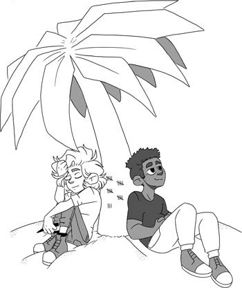

穴居人的时代，大规模计算的需求不大。因此，在墙上画几道线，或把一些松果堆在一起，就能满足记录数目的需求。但应用稍微复杂一点，就会发现这种一元记数系统的问题。站在今天更先进的立场上，不仅难以区分记录数字零与根本没有记录任何特定东西，而且用这样的数进行算术运算也很低效。不过，本章将带我们回到原始的一元数，定义各种函数并证明一些引理。In the days of cave dwellers, the need for doing large calculations was not big. Therefore, some lines drawn on a wall or some pine cones collected in a pile could address the demand for recording numbers. For even slightly more sophisticated applications, we find problems with such unary numbering systems. With our improved state today, we would see a problem not only in the diﬃculty to distinguish recording the number zero from not having recorded anything in particular, but also in the ineﬃcient ways of doing arithmetic on such numbers. Nevertheless, in this chapter I will take us back to the primitive unary numbers to define various functions and prove some lemmas.

## 7.0. 基本定义7.0. Basic Definitions

一元数归纳定义如下：The unary numbers are defined inductively:

**datatype** Unary = Zero | Suc(pred: Unary)

可以看到，一元数要么是零，要么是另一个一元数的后继。定义新数据类型时，并不总能幸运地将它与另一种等价表示联系起来，通常必须证明所定义的东西具有所需性质。不过，对于一元数，可以直接给出它与自然数之间双向的转换函数：As you can see, a unary number is either zero or the successor of some other unary number. When we define a new datatype, we don't always have the luxury to link it with another equivalent representation. Instead, we often have to prove that what we have defined has the properties we want. But in the case of the unary numbers, we can directly give conversion functions to and from the natural numbers:

**function** UnaryToNat(x: Unary): **nat** {

**match** x

**case** Zero => 0

**case** Suc(x’) => 1 + UnaryToNat(x’)

}

**function** NatToUnary(n: **nat**): Unary {

**if** n == 0 **then** Zero **else** Suc(NatToUnary(n-1))

}

由这些定义，很容易证明一元数与自然数一一对应。也就是说，证明每个方向的转换函数都是单射。From these definitions, it is easy to prove that the unary numbers and natural numbers are in one-to-one correspondence with each other. That is, we prove that the conversion function in each direction is injective.

**lemma** NatUnaryCorrespondence(n: **nat**, x: Unary)

**ensures** UnaryToNat(NatToUnary(n)) == n

**ensures** NatToUnary(UnaryToNat(x)) == x

{

}

## 习题7.0。Exercise 7.0.

故意不合理地修改UnaryToNat和NatToUnary主体，使单射性被破坏，即使引理NatUnaryCorrespondence变为假。Nonsensically change the bodies of UnaryToNat and NatToUnary in a way that breaks injectivity, that is, that renders lemma NatUnaryCorrespondence false.

本章将用这些函数证明，我们定义的一元数操作确实对应自然数上的类似操作，例如Add对应+。这些性质将以名称形如…Correct的引理给出。本章的全部目的就是使用Unary而非Dafny内置的**nat**，因此不要将这些转换函数或引理NatUnaryCorrespondence用于任何其他用途。In this chapter, I will use these functions to prove that the operations we define on unary numbers do indeed correspond to the analogous operations on the natural numbers, for example, that Add corresponds to +. These properties will be given in lemmas with names of the form …Correct. The whole point of this chapter is to get to work with Unary rather than Dafny's built-in **nat**, so let's not use these conversion functions or the NatUnaryCorrespondence lemma for anything else.

## 7.1. 比较7.1. Comparisons

一元数上的第一种操作是比较。Our first operation on unary numbers is a comparison.

**predicate** Less(x: Unary, y: Unary) {

y != Zero && (x.Suc? ==> Less(x.pred, y.pred))

}

此定义表示，x（严格）小于y，当且仅当y非零，并且如果x也非零，则x的前驱小于y的前驱。如第4.2节所述，当然也可以用具有两个分支的**match**表达式定义Less。就个人喜好而言，我觉得这里给出的定义更直接。This definition says that x is (strictly) less than y exactly when y is non-zero and, furthermore, if x is also non-zero, then the predecessor of x is less than the predecessor of y. As mentioned in Section 4.2, of course you could also define Less using a **match** expression with two cases. To my taste, I find the definition I gave here to be more straightforward.

## 习题7.1。Exercise 7.1.

使用**match**表达式定义谓词Less’。证明它与上面的Less等价。Using a **match** expression, define a predicate Less’. Prove that it is equivalent to Less above.

## 习题7.2。Exercise 7.2.

定义Less，但不使用**match**、判别器Suc?或蕴含运算符==>。Define Less without a **match**, without using the discriminator Suc?, and without using the implication operator, ==>.

为确认定义的确是正确的序，编写以下引理，它会被自动证明：To prove to ourselves that we have defined the correct ordering, we write the following lemma, which is proved automatically:

**lemma** LessCorrect(x: Unary, y: Unary)

**ensures** Less(x, y) <==> UnaryToNat(x) < UnaryToNat(y)

{

}

注意，引理后置条件使用布尔等价运算符（“当且仅当”，其结合强度低于所有其他二元运算符）。也可以使用布尔相等运算符：Note that the lemma postcondition uses the equivalence operator on booleans (“if and only if”, whose binding power is lower than that of any other binary operator). Alternatively, we could have used the equality operator of booleans:

**ensures** Less(x, y) == (UnaryToNat(x) < UnaryToNat(y))

但是，与==不同，运算符<==>的优先级低于<，因此第一种写法省了一对括号。However, unlike ==, operator <==> has lower operator precedence than <, so we save a pair of parentheses in the first formulation.

接下来证明Less具有*传递性*。以下是陈述并证明该性质的一种方式：Next, we show that Less has the property of being *transitive*. Here is one way to state and prove the property:

**lemma** LessTransitive(x: Unary, y: Unary, z: Unary)

**requires** Less(x, y) && Less(y, z)

**ensures** Less(x, z)

{

}

引理有前件时，例如这里的Less(x, y) && Less(y, z)，通常最好将前件写入**requires**子句。这样，客户调用引理时若未确立前置条件，调用处就会报错。但是，对于传递性，我们可能希望允许客户从不同方向使用该性质，例如由Less(x, y)和!Less(x, z)确立!Less(y, z)。因此，最好不设前置条件，而在后置条件中使用蕴含来陈述此引理。Often when a lemma has an antecedent, like Less(x, y) && Less(y, z) in this case, it is better to write the antecedent in a **requires** clause. This way, if a client fails to establish the precondition when calling the lemma, the call gets flagged with an error. However, for the transitivity property, we may want to allow a client to use the property in a different direction, for example to establish !Less(y, z) from Less(x, y) and !Less(x, z). Therefore, it is better to state this lemma without a precondition and instead with an implication in the postcondition.

**lemma** LessTransitive(x: Unary, y: Unary, z: Unary)

**ensures** Less(x, y) && Less(y, z) ==> Less(x, z)

## 边栏7.0Sidebar 7.0

Dafny的许多运算符可以根据宽度判断相对优先级：越宽的运算符优先级越低。宽4个字符的<==>优先级最低。宽3个字符的==>和<==结合更紧密，宽2个字符的&&和||又更紧密。比较运算符结合得更紧密，尽管宽度有1个也有2个字符：==、!=、<=、<、>和>=。单字符运算符比它们更紧密，首先是加法类运算符+和-，然后是乘法类运算符*、/和%，最后是结合最紧密的按位运算符&、|和∧。For many operators in Dafny, you can tell its relative operator precedence from its width: a wider operator has lower precedence. The 4-characters-wide operator <==> has the lowest precedence. The 3-characters-wide operators ==> and <== bind more tightly, and the 2-characters-wide operators && and || bind more tightly yet. Comparison operators bind even more tightly, though their widths are both 1 and 2 characters: ==, !=, <=, <, >, and >=. Single-character operators bind tighter than these, first the additive operators + and -, then the multiplicative operators *, /, and %, and finally, most strongly, the bitwise operators &, |, and ∧.

或许出人意料，这个版本的引理不能自动证明。无需理解自动化为何失败，不妨直接编写证明，从中学习有益的要点。要在以下假设下证明Less(x, z)：Perhaps surprisingly, this version of the lemma is not proved automatically. It is not necessary to understand why automation fails. Instead, let us just write the proof, which will illustrate good learning points. We are proving Less(x, z) under the assumption of

Less(x, y) && Less(y, z)

为在证明中引入此假设，使用条件语句：To introduce this assumption in our proof, we use a conditional statement:

{

**if** Less(x, y) && Less(y, z) {

然后在then分支编写证明。与通常编程一样，进入then分支时，可以假定所述条件成立。else分支没有需要证明的内容，因为若Less(x, y) && Less(y, z)不成立，引理便平凡成立。and write the proof in the then branch. As usual in programming, we get to assume the stated condition to hold upon entering the then branch. In the else branch, there is nothing for us to prove, since the lemma holds trivially if Less(x, y) && Less(y, z) does not hold.

要在then分支内证明Less(x, z)，注意Less(x, z)的定义包含两个合取项。因此，要证明Less(x, z)，就必须证明两个合取项。第一个是z != Zero，直接由Less(y, z)定义中的同一合取项得到。另一个是蕴含，因此用另一个**if**语句继续证明：To prove Less(x, z) inside the then branch, we note that the definition of Less(x, z) consists of two conjuncts. So, to prove Less(x, z), we'll have to prove both of those conjuncts. The first conjunct is z != Zero, which follows directly from the same conjunct in the definition of Less(y, z). The other conjunct is an implication, so we continue the proof with yet another **if** statement:

**if** x.Suc? {

根据Less定义，外层if守卫蕴含y和z非零，内层if守卫给出额外假设：x非零。因此，可以对x、y和z的前驱递归调用引理。换言之，对这些前驱应用归纳假设：By the definition of Less, the outer if guard implies that y and z are non-zero, and the inner if guard gives us the additional assumption that x is non-zero. This means we can call the lemma recursively on the predecessors of x, y, and z. In other words, we invoke the induction hypothesis on these predecessors:

LessTransitive(x.pred, y.pred, z.pred);

}

}

}

显然，Dafny能补齐其余衔接步骤，证明至此完成。Evidently, Dafny can fill in the remaining proof glue, so this completes the proof.

## 习题7.3。Exercise 7.3.

陈述并证明Less具有三歧性的引理，即以下条件*恰有一个*成立：Less(x, y), x == y, Less(y, x)。（记住，这里以及本章其他地方，都不要让证明依赖将Unary转换成**nat**。）State and prove a lemma that Less is trichotomous, that is, that *exactly one* of the following holds: Less(x, y), x == y, Less(y, x). (Remember here and elsewhere in this chapter, do not let your proof depend on the conversion of Unary to **nat**.)

## 习题7.4。Exercise 7.4.

将谓词Below(x, y)定义为Less(x, y) || x == y。陈述并证明Below是*全序*，即它具有自反性、传递性、反对称性（Below(x, y) && Below(y, x)蕴含x == y）和完全性（Below(x, y) || Below(y, x)）。Define a predicate Below(x, y) as Less(x, y) || x == y. State and prove that Below is a *total order*, that is, that it is reflexive, transitive, antisymmetric (Below(x, y) && Below(y, x) implies x == y), and total (Below(x, y) || Below(y, x)).

## 7.2. 加法与减法7.2. Addition and Subtraction

两个一元数的加法由递归函数Add定义：The addition of two unary numbers is defined by a recursive function Add:

**function** Add(x: Unary, y: Unary): Unary {

**match** y

**case** Zero => x

**case** Suc(y’) => Suc(Add(x, y’))

}

此函数对应自然数加法，如以下引理所示。This function corresponds to addition on natural numbers, as the following lemma shows.

**lemma** AddCorrect(x: Unary, y: Unary)

**ensures** UnaryToNat(Add(x, y)) == UnaryToNat(x) + UnaryToNat(y)

{

}

Add(x, y)的定义按y的不同情况展开。这立即给出性质Suc(Add(x, y)) == Add(x, Suc(y))。换言之，Suc对Add的第二个实参满足分配律。Suc对Add的第一个实参也满足分配律，但此性质需要归纳证明：The definition of Add(x, y) proceeds by considering different cases for y. This immediately gives us the property Suc(Add(x, y)) == Add(x, Suc(y)). In other words, Suc distributes over the second argument of Add. Suc also distributes over the first argument of Add, but this property requires an inductive proof:

**lemma** SucAdd(x: Unary, y: Unary)

**ensures** Suc(Add(x, y)) == Add(Suc(x), y)

{

}

Add的定义立即给出Zero是Add的右单位元（即对任意x都有Add(x, Zero) == x）。下面证明Zero也是左单位元：The definition of Add immediately gives us that Zero is a right unit element of Add (that is, Add(x, Zero) == x for any x). Here is a proof that Zero is also a left unit element:

**lemma** AddZero(x: Unary)

**ensures** Add(Zero, x) == x

{

}

## 习题7.5。Exercise 7.5.

关闭自动归纳，为(a) AddCorrect、(b) SucAdd以及(c) AddZero编写证明。Turn off automatic induction and write proofs for (a) AddCorrect, (b) SucAdd, and (c) AddZero.

## 习题7.6。Exercise 7.6.

证明Add满足结合律：Prove that Add is associative:

Add(Add(x, y), z) == Add(x, Add(y, z))

## 习题7.7。Exercise 7.7.

证明Add满足交换律：Add(x, y) == Add(y, x)。Prove that Add is commutative: Add(x, y) == Add(y, x).

## 习题7.8。Exercise 7.8.

证明以下引理，它陈述结合律与交换律的组合：Prove the following lemma, which states a combination of associativity and commutativity:

**lemma** AddCommAssoc(x: Unary, y: Unary, z: Unary)

**ensures** Add(Add(x, y), z) == Add(Add(x, z), y)

也定义一个一元数减法函数。由于没有负的一元数，仅在x至少与y一样大时定义Sub(x, y)。We also define a function for subtracting unary numbers. Since we do not have any negative unary numbers, we define Sub(x, y) only when x is at least as large as y.

**function** Sub(x: Unary, y: Unary): Unary

**requires** !Less(x, y)

{

**match** y

**case** Zero => x

**case** Suc(y’) => Sub(x.pred, y’)

}

**lemma** SubCorrect(x: Unary, y: Unary)

**requires** !Less(x, y)

**ensures** UnaryToNat(Sub(x, y)) == UnaryToNat(x) - UnaryToNat(y)

{

}

## 习题7.9。Exercise 7.9.

为以下引理编写合适的前置条件，再证明引理。Write a suitable precondition for the following lemma. Then prove the lemma.

**lemma** AddSub(x: Unary, y: Unary)

// requires ?

**ensures** Add(Sub(x, y), y) == x

## 7.3. 乘法7.3. Multiplication

对于一元数，乘法定义为反复相加。For unary numbers, multiplication is defined by repeated addition.

**function** Mul(x: Unary, y: Unary): Unary {

**match** x

**case** Zero => Zero

**case** Suc(x’) => Add(Mul(x’, y), y)

}

与其他操作类似，证明Mul对应自然数上的*。这次证明需要一些人工协助。Analogous to what we did for the other operation, we prove that Mul corresponds to * on the natural numbers. This time, the proof requires a little assistance from us.

**lemma** MulCorrect(x: Unary, y: Unary)

**ensures** UnaryToNat(Mul(x, y)) == UnaryToNat(x) * UnaryToNat(y)

{

**match** x

**case** Zero =>

**case** Suc(x’) =>

**calc** {

UnaryToNat(Mul(x, y));

== // def. Mul

UnaryToNat(Add(Mul(x’, y), y));

== { AddCorrect(Mul(x’, y), y); }

UnaryToNat(Mul(x’, y)) + UnaryToNat(y);

// Dafny can take it from here on

}

}

## 7.4. 除法与模7.4. Division and Modulus

接下来定义除法与模（余数）时，会遇到几个值得学习的要点。一元数的除法与模通过反复相减实现。由于这两个操作执行类似计算，将它们封装进同一函数。因此，所定义的函数将返回一个*有序对*。对于任意类型A和B，由一个A值和一个B值组成的有序对类型，在Dafny中记作(A, B)。Next up, as we define division and modulus (remainder), we encounter several teaching points. For unary numbers, division and modulus are done by repeated subtraction. Since the two operations perform similar computations, we will package them both in one function. The function we define will therefore return a *pair*. For any types A and B, the type representing pairs with one A value and one B value is denoted (A, B) in Dafny.

**function** DivMod(x: Unary, y: Unary): (Unary, Unary)

约定返回的有序对的第一个分量是x除以y的商，第二个分量是其模。构造d与m的有序对的记法就是(d, m)。两个分量各自的解构器称为0和1，因此若r是DivMod(x, y)返回的有序对，r.0表示x除以y的商，r.1表示其模。Our convention will be that the first component of the returned pair is the division of x by y and the second component is their modulus. The notation for constructing a pair of d and m is simply (d, m). The destructors for the two respective components are called 0 and 1, so if r is the pair returned by DivMod(x, y), then r.0 denotes the division of x by y and r.1 denotes their modulus.

仅对非零除数定义函数：We define our function only for non-zero divisors:

**requires** y != Zero

DivMod的一个直接定义似乎如下：A straightforward definition of DivMod would seem to be the following:

{

**if** Less(x, y) **then**

(Zero, x)

**else**

**var** r := DivMod(Sub(x, y), y); // cannot prove termination

(Suc(r.0), r.1)

}

但是，Dafny无法自动证明DivMod的递归调用终止。看看帮助验证器证明终止性的两种不同方法。However, Dafny is not automatically able to prove that the recursive call to DivMod terminates. Let's look at two different ways to help the verifier along to prove termination.

### 7.4.0. 通过自然数证明终止性7.4.0. Termination via natural numbers

要证明终止性，需要采用一种能证明在每次递归调用时都减小的终止性度量。DivMod(x, y)调用DivMod(Sub(x, y), y)，因此唯一选择是证明第一个实参的某个量减小。解释成自然数时，由于已知y非零，UnaryToNat(x) - UnaryToNat(y)小于UnaryToNat(x)。为了表明使用x对应的自然数作为终止性度量，声明自己的**decreases**子句：To prove termination, we need to use a termination metric that we can show to decrease with every recursive call. We have that DivMod(x, y) calls DivMod(Sub(x, y), y), so our only choice is to show that something about the first argument decreases. Interpreted as natural numbers, we have that UnaryToNat(x) - UnaryToNat(y) is less than UnaryToNat(x), since y is known to be non-zero. To say that we want to use the natural number corresponding to x as our termination metric, we declare our own **decreases** clause:

**decreases** UnaryToNat(x)

现在，要证明递归调用终止，需要证明To prove termination of the recursive call, we now need to prove

UnaryToNat(x) ≻ UnaryToNat(Sub(x, y))

由于UnaryToNat的结果类型是**nat**，该条件就是Since UnaryToNat results in a **nat**, this condition is

UnaryToNat(Sub(x, y)) < UnaryToNat(x)

遗憾的是，这也不能自动完成。Alas, this is not done automatically, either.

为进一步帮助验证器，可以调用引理SubCorrect，它说明该不等式左侧等于To help the verifier some more, we can invoke the SubCorrect lemma, which says the left-hand side of this inequality is equal to

UnaryToNat(x) - UnaryToNat(y)

将这个引理调用插在let表达式之前：We insert this lemma call just before the let expression:

SubCorrect(x, y);

**var** r := DivMod(Sub(x, y), y);

这个引理调用在源文本中独占一行很合适。如果愿意，也可以把它移得更靠近需要它的位置：The lemma call fits nicely on this line by itself in the source text. If we wanted to, we could move it even closer to the place where it is needed:

**var** r := (SubCorrect(x, y); DivMod(Sub(x, y), y));

注意，此处需要额外括号，使语法分析器不至于仅将SubCorrect(x, y)作为let绑定的右侧。Note the need for the extra parentheses in this case, so that the parser does not just take SubCorrect(x, y) as the right-hand side of the let binding.

事实上，还可以把引理调用移得更近。例如：In fact, we can move the lemma call even closer yet. For example:

**var** r := DivMod(SubCorrect(x, y); Sub(x, y), y);

重要的是，在验证器检查DivMod调用的前置条件与终止性之前，先向它提供引理的信息；该检查发生在调用参数求值之后。通常应把引理放在需要它的位置附近，但没必要过头，因此我喜欢把它独占一行放在let之前。The important thing is to give the verifier the lemma's information before it checks the precondition and termination of the call to DivMod, which happens after the evaluation of the call's parameters. It is generally desirable to place a lemma close to where it is needed, but there is no reason to go overboard, so I like the placement on a line by itself before the let.

### 7.4.1. 通过结构包含证明终止性7.4.1. Termination via structural inclusion

由于这里恰好有与自然数的对应关系，在终止性证明中使用UnaryToNat和SubCorrect相当容易。但这不是唯一办法。另一种方法是更直接地论证，Sub(x, y)返回的数据类型值在结构上小于x。换言之，如果把一元数想象成洞穴墙上画的线，那么Sub(x, y)就是比x更短的线条序列。Dafny知道，传给构造器的数据类型参数在结构上小于构造器的返回值。要使它理解此性质还具有传递性，需要证明一个引理：Since we happened to have the correspondence with natural numbers in this case, it was easy enough to use UnaryToNat and SubCorrect in the termination proof. But this is not the only way we can do it. Another way is to argue more directly that the datatype value returned by Sub(x, y) is structurally smaller than x. Stated differently, if you think of unary numbers as being scribbled as lines on the wall of a cave, then Sub(x, y) is a shorter sequence of lines than x. Dafny knows that the datatype parameters to a constructor are structurally smaller than what the constructor returns. To get it to understand that this property also holds transitively, we need to prove a lemma:

**lemma** SubStructurallySmaller(x: Unary, y: Unary)

**requires** !Less(x, y) && y != Zero

**ensures** Sub(x, y) < x

{

}

在Dafny中，<运算符被重载，可作用于多种实参类型。在此引理的后置条件中，它作用于数据类型值，因此表示结构包含。这个引理通过归纳自动证明。In Dafny, the < operator is overloaded to work on various argument types. In the post-condition of this lemma, it works on datatype values and thus stands for structural inclusion. This lemma is proved automatically by induction.

现在只需在DivMod的let表达式前调用引理。以下是DivMod的完整定义：All we have to do now is call the lemma before the let expression in DivMod. Here is the full definition of DivMod:

**function** DivMod(x: Unary, y: Unary): (Unary, Unary)

**requires** y != Zero

{

**if** Less(x, y) **then**

(Zero, x)

**else**

SubStructurallySmaller(x, y);

**var** r := DivMod(Sub(x, y), y);

(Suc(r.0), r.1)

}

第6.2节讨论过，以内在和外在方式陈述并证明函数性质的区别。在Dafny中，函数（以及方法）的终止性必须始终以内在方式处理。也就是说，不允许先声明函数、忽略终止性，再尝试在单独的引理中证明终止性；必须在函数声明本身中证明终止性（可以借助额外引理，如上面的SubCorrect和SubStructurallySmaller所示）。In Section 6.2, I discussed intrinsic versus extrinsic ways of stating and proving properties of functions. Termination of functions (and of methods, too) must always be done intrinsically in Dafny. That is, you are not allowed to declare a function, ignore termination, and try to prove termination later in a separate lemma—termination must be proved in the function declaration itself (possibly with the help of additional lemmas, as illustrated by SubCorrect and SubStructurallySmaller above).

### 7.4.2. 带模式的let表达式7.4.2. Let expressions with patterns

调整DivMod定义时，也借此机会介绍另一个方便的语言特性。let表达式左侧可以是模式，很像**match**的各个分支。例如，若F(e)是已知返回非零一元数的函数，就可以把模式Suc(w)放在let左侧。这会把w绑定为F(e)返回的Suc值的参数。换言之，先计算F(e)的值，再“剥去”该值最外层的Suc，将剩余部分绑定给w。要做到这一点，必须知道F(e)确实返回Suc而非Zero。因此，经过以下两个let绑定While we are tweaking the definition of DivMod, this gives me the opportunity to introduce another convenient language feature. The left-hand side of a let expression can be a pattern, much like the cases of a **match**. For example, if F(e) is a function that is known to return a non-zero unary number, then we can use the pattern Suc(w) as the left-hand side of the let. This will bind w to the parameter of the Suc value returned by F(e). In other words, it will compute the value of F(e), then “shave off” the outermost Suc of that value, and then bind what remains to w. For this to work, it must be known that F(e) does indeed return a Suc, not Zero. So, after the following two let bindings

**var** r := F(e);

**var** Suc(w) := F(e);

就有r == Suc(w) 和r.pred == w。we have r == Suc(w) and r.pred == w.

有序对是具有特殊语法的内置数据类型。特别是，它唯一的构造器只用括号表示。因此，在let表达式中使用模式，可将DivMod最后两行写为：A pair is a built-in datatype with special syntax. In particular, its sole constructor is written with just parentheses. Using a pattern in the let expression, we can therefore write the last two lines of DivMod as follows:

**var** (d, m) := DivMod(Sub(x, y), y);

(Suc(d), m)

最后，注意这个let与如下错误表达式之间的细微差别：这个let把d和m绑定到DivMod返回的同一个有序对的不同分量，而错误表达式Finally, note the subtle difference between this let, which binds d and m to the different components of the one pair returned by DivMod, and an incorrect expression

**var** d, m := DivMod(Sub(x, y), y); // error

有*两个*左侧（d和m），却只有一个右侧（对DivMod的调用）。where there are *two* left-hand sides (d and m) and only one right-hand side (the call to DivMod).

### 7.4.3. DivMod的正确性7.4.3. Correctness of DivMod

本章最后证明DivMod确实正确。不过，不通过自然数证明正确性，而是证明除法和模满足预期性质。对于任意自然数a和正整数b，性质如下：I'll wrap up this chapter with a proof that DivMod is really correct. But instead of proving correctness via the natural numbers, let us prove that division and modulus satisfy the properties we expect. These properties are as follows, for any natural number a and positive integer b:

(a / b) * b + (a % b) == a

(a % b) < b

（这里所有括号都是多余的，添加它们只是为了突出除法和模运算的位置。）将其陈述为关于一元数的引理，就得到：(All of the parentheses here are unnecessary. I added them to emphasize where the division and modulus operations are.) Stated as a lemma about the unary numbers, we have:

**lemma** DivModCorrect(x: Unary, y: Unary)

**requires** y != Zero

**ensures var** (d, m) := DivMod(x, y);

Add(Mul(d, y), m) == x &&

Less(m, y)

注意，在此引理后置条件中使用let表达式十分方便，可以给DivMod返回的内容命名。Note how it was convenient to use a let expression in the postcondition of this lemma, so that we can give names to what is returned by DivMod.

证明先引入局部变量（与后置条件内部的绑定变量同名），表示将要证明性质的一元数。We start the proof by introducing local variables (with the same names as the bound variables inside the postcondition) to stand for the unary numbers we are going to prove the properties of.

{

**var** (d, m) := DivMod(x, y);

接着遵循DivMod定义中的两个分支。虽然证明不必如此，但可以使用**assert**语句，提醒自己DivMod在此分支返回什么。Next, we will follow the two cases in the definition of DivMod. Although it is not necessary for the proof, we can use an **assert** statement to remind ourselves of what DivMod returns in this case.

**if** Less(x, y) {

**assert** d == Zero && m == x; // since (d, m) == DivMod(x, y)

这里立即得到Less(m, y)。此分支其余部分是一段简单演算：Here, we immediately have Less(m, y). The rest of this case is a simple calculation:

**calc** {

Add(Mul(d, y), m) == x;

== // d, m

Add(Mul(Zero, y), x) == x;

== // def. Mul

Add(Zero, x) == x;

== { AddZero(x); }

**true**;

}

对于另一分支，先给DivMod递归调用的返回值命名，再用**assert**提醒自己DivMod(x, y)在此分支返回什么。For the other case, we start by introducing names for what is returned by the recursive call to DivMod, and we use an **assert** to remind ourselves of what DivMod(x, y) returns in this case.

} **else** {

**var** (d’, m’) := DivMod(Sub(x, y), y);

**assert** d == Suc(d’) && m == m’; // since (d, m) == DivMod(x, y)

继续证明有多种方式。通常从证明目标较复杂的一侧开始演算，因为这样提供更多结构，有助于找出证明步骤。这次换个方式，从结构丰富程度另一极端的公式——字面量**true**——开始。There are several ways to proceed. We usually start a proof calculation with the more complicated side of the proof goal, because this gives us more structure that may help us in figuring out the proof steps. Let us do it differently in this case and start with a formula at the opposite end of the spectrum of structurally rich formulas, the literal **true**.

**calc** {

**true**;

这似乎有些自虐，但再走一步就能看出方向：下一步引入归纳假设提供的性质。This seems rather masochistic, but after one more step we will see where this is going: the next step is to introduce the properties gained by the induction hypothesis.

==> { SubStructurallySmaller(x, y);

DivModCorrect(Sub(x, y), y); }

Add(Mul(d’, y), m) == Sub(x, y) && Less(m, y);

注意，为证明DivModCorrect递归调用的终止性，先在演算提示中调用SubStructurallySmaller引理。从左边的演算连接符也能看出，目标是形如**true** ==> *proof goal*的证明。剩余证明很直接，使用习题7.9和7.8中证明的引理：Note that to prove termination of the recursive call to DivModCorrect, we first invoke the SubStructurallySmaller lemma in the calculation hint. You can also tell from the calculation connective in the left margin that we are going for a proof of the form **true** ==> *proof goal*. The rest of the proof is straightforward, using the lemmas proved in Exercises 7.9 and 7.8:

==> // add y to both sides

Add(Add(Mul(d’, y), m), y) == Add(Sub(x, y), y) &&

Less(m, y);

== { AddSub(x, y); }

Add(Add(Mul(d’, y), m), y) == x && Less(m, y);

== { AddCommAssoc(Mul(d’, y), m, y); }

Add(Add(Mul(d’, y), y), m) == x && Less(m, y);

== // def. Mul, d

Add(Mul(d, y), m) == x && Less(m, y);

}

}

}

## 7.5. 小结7.5. Summary

本章主要是练习证明简单数据类型上函数性质的练习场，但也遇到了几个要点：This chapter has mostly been a playground to practice proving properties of functions on a simple datatype. But we also came across several important points:

对于许多递归函数，如何分解参数供递归调用使用，以及如何从递归调用构建结果，都有选择。这种选择会使某些函数性质显然易证，而类似的其他性质却可能需要归纳证明。例如，如果通过分解第一个参数定义Add，定义会平凡地表明Zero是Add的左单位元，而证明Zero是右单位元就需要归纳证明（使用引理）。如果改为分解第二个参数定义Add，则左单位元性质需要归纳，而右单位元性质直接由定义得出。应当意识到这种不对称带来的取舍。第6.2.0节的Append也有这种不对称性，第12.2和12.3节还将遇到相关问题。For many recursive functions, there's a choice in how to decompose the parameters for the recursive call and how to build the result from the recursive call. This choice will make some properties of the function trivial to prove, while similar properties may require a proof by induction. For example, if you define Add by decomposing its first parameter, the definition trivially shows that Zero is a left unit of Add, whereas you'll need an inductive proof (using a lemma) to show that Zero is a right unit. If you instead define Add by decomposing its second parameter, you'll need induction for the left-unit property, whereas the right-unit property follows trivially from the definition. It's a good idea to be aware of the trade-offs with this asymmetry. We have also seen this asymmetry with Append in Section 6.2.0, and we'll see related issues in Sections 12.2 and 12.3.

本章还进一步学习了终止性。许多终止性证明是自动完成的，甚至终止性度量也自动指定，但有时必须手工编写证明。在Dafny中，函数终止性度量通常是函数参数列表（组成的字典序元组），但通过手工提供**decreases**子句，可以使用由参数计算出的任意值列表。验证工具（包括Dafny）通常要求以内在方式证明函数终止性，即必须作为函数定义本身的一部分确立终止性。In this chapter, we also learned more about termination. While many termination proofs are automatic, even to the degree that specifying the termination metric is automatic, we sometimes have to write termination proofs manually. In Dafny, the termination metric for a function is usually (the lexicographic tuple consisting of) the function's list of parameters, but by manually supplying a **decreases** clause, you can make the termination metric be any list of values computed from the parameters. It is common in verification tools (including Dafny) to require the termination of a function to be proved intrinsically; that is, termination must be established as part of the function definition itself.

定义于数据类型的函数常使用结构包含证明终止性。验证器会自动考虑直接结构包含，但要获得传递的结构包含，可能需要证明引理。Functions defined on datatypes often use structural inclusion to prove termination. While direct structural inclusion is automatically considered by the verifier, you may need to prove a lemma to obtain transitive structural inclusion.

要证明P ==> Q这样的性质，通常编写如下形式的证明：To prove a property like P ==> Q, you often write a proof of the form

**if** P {

// prove Q here

}

## 注释Notes

函数UnaryToNat和NatToUnary展示了Unary类型值与自然数一一对应。用Unary这样具有构造器Zero和Suc的归纳数据类型表示自然数的思路，直接来自Giuseppe Peano提出的自然数*公理化*。因此，一元数集合——更确切地说，自然数的Zero/Suc表示——通常称为皮亚诺数。Our UnaryToNat and NatToUnary functions demonstrate that there is a one-to-one correspondence between the values of type Unary and the natural numbers. The idea to represent the natural numbers by an inductive datatype like Unary, with constructors Zero and Suc, follows directly from an *axiomatization* of the natural numbers that was developed by Giuseppe Peano. Therefore, the set of unary numbers—more precisely, the Zero/Suc representation of the natural numbers—is often known as Peano numbers.

由于皮亚诺数用如此简单的归纳数据类型描述，它们是形式化证明中很受欢迎的研究对象。Because the Peano numbers are described by such a simple inductive datatype, they are popular as a subject of formal proofs.

# 第8章 排序Chapter 8 Sorting

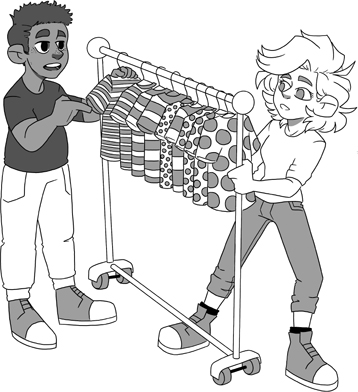

排序是计算机科学中经常出现的主题。本章关注两个列表排序算法的正确性。数据类型List及Length等各种列表函数沿用第6章。An often occurring theme in computer science is that of sorting. This chapter is concerned with the correctness of two sorting algorithms that operate on lists. The datatype List and various functions on lists, such as Length, are those from Chapter 6.

本章开始把最终希望编译的主要算法函数，与只用于规约的辅助函数分开。这些仅用于规约的函数将声明为**ghost**。In this chapter, I will start to separate the main algorithmic functions, which we eventually want to compile, from the supporting functions used only in specifications. These specification-only functions will be declared as **ghost**.

## 8.0. 规约8.0. Specification

先考虑排序的规约。显然，希望排序例程的输出有序。We start by considering the specification of sorting. Obviously, we want the output of our sorting routines to be ordered.

### 8.0.0. 有序8.0.0. Sorted

整数列表有序，意味着元素按数值升序排列。处理列表时，最容易表达此性质的方法，是说列表中任意两个相邻元素都有序。For a list of integers to be sorted means that the elements are in ascending numerical order. When we work with lists, this property is most easily expressed by saying that any two consecutive elements of the list are ordered.

**ghost predicate** Ordered(xs: List<**int**>) {

**match** xs

**case** Nil => **true**

**case** Cons(x, Nil) => **true**

**case** Cons(x, Cons(y, _)) => x <= y && Ordered(xs.tail)

}

共有三个分支。前两个分别适用于空列表和单元素列表，它们总是有序。第二个分支在Cons模式内部使用构造器Nil，这是嵌套模式，当xs是表尾为Nil的Cons时匹配。如果此分支适用，x绑定为xs表头，供**case**构造主体使用。第三个分支也使用嵌套模式，当xs和xs表尾均为Cons值时匹配；若适用，x和y分别绑定为xs.head和xs.tail.head。与通常的模式一样，xs.tail.tail位置的下划线表示不想引入任何绑定变量来代表该子表达式。当xs前两个元素有序且xs.tail元素两两有序时，第三个分支主体的求值结果为**true**。There are three cases. The first two apply to the empty list and to singleton lists, respectively, which are always sorted. The use of the constructor Nil inside the Cons pattern in the second case is a nested pattern, which matches when xs is a Cons whose tail is Nil. If the case applies, then x is bound to the head of xs for use in the body of the **case** construct. The third case also uses a nested pattern. It matches when both xs and the tail of xs are Cons values, and if the case applies, then x and y are bound to xs.head and xs.tail.head, respectively. As usual in patterns, the underscore in the position of xs.tail.tail says that we don't care to introduce any bound variable to stand for that subexpression. The body of the third case evaluates to **true** when the first two elements of xs are ordered and the elements of xs.tail are pairwise ordered.

如果觉得像这里的Ordered这样的定义复杂或不直观，最好验证它具有某些预期性质。对于满足Ordered的列表，预期列表中任意靠前元素都不大于任意靠后元素。利用获取列表特定元素的列表函数At（第6.4节），可精确陈述此性质，从而得到以下引理：If you feel that a definition, like Ordered here, is complicated or non-obvious, it is a good idea to verify that it has some properties that we expect it to have. For a list that satisfies Ordered, we expect that any element earlier in the list is below any element later in the list. We can state this precisely using the list function At (from Section 6.4), which retrieves a particular element of the list. That leads us to the following lemma:

**lemma** AllOrdered(xs: List<**int**>, i: **nat**, j: **nat**)

**requires** Ordered(xs) && i <= j < Length(xs)

**ensures** At(xs, i) <= At(xs, j)

引理不能自动证明，因此编写证明帮助验证器。根据At定义，如果i非零（由AllOrdered前置条件可知，这蕴含j也非零），证明目标就等价于The proof of this lemma does not go through automatically, so let's help the verifier along by writing the proof. By the definition of At, if i is non-zero (which, by AllOrdered's precondition, implies that j is non-zero, too), then our proof goal is equivalent to

At(xs.tail, i - 1) <= At(xs.tail, j - 1)

因此，AllOrdered的证明这样开始：so we start our proof of AllOrdered as follows:

{

**if** i != 0 {

AllOrdered(xs.tail, i - 1, j - 1);

如果i是0，则需论证：沿列表向后寻找位置j处的元素，得到的元素不小于xs表头。如果j也是0，这显然成立：If i is 0, then we need to argue that going down the list until we find the element at position j gives us an element that is no smaller than the head of xs. This is trivial if j is also 0:

} **else if** i == j {

如果j非零，性质可由下式推出：If j is non-zero, then the property follows from

At(xs, 0) <= At(xs, 1) <= At(xs, j)

列表有序这一事实给出条件At(xs, 0) <= At(xs, 1)。条件At(xs, 1) <= At(xs, j)等价于At(xs.tail, 0) <= At(xs.tail, j - 1)，因此可递归调用引理，由归纳假设获得。于是AllOrdered的证明以下列方式结束：We get the condition At(xs, 0) <= At(xs, 1) from the fact that the list is ordered. The condition At(xs, 1) <= At(xs, j) is equivalent to At(xs.tail, 0) <= At(xs.tail, j - 1), which means we can obtain it from the induction hypothesis by calling the lemma recursively. Our proof of AllOrdered thus comes to an end like this:

} **else** {

AllOrdered(xs.tail, 0, j - 1);

}

}

现在可以相当有把握地认为，正确陈述了性质Ordered。We can now feel reasonably confident that we have stated the property Ordered correctly.

### 8.0.1. 相同元素8.0.1. Same elements

并非每个输出有序元素列表的函数都是排序例程。还希望描述输入元素与输出元素之间的某种关系。首先，希望输出恰好由输入中的*相同元素*组成，但排列顺序可以不同。这样定义此性质：对于任意元素p，p在输入中的出现次数等于p在输出中的出现次数。换言之，输入元素的*多重集*等于输出元素的多重集。多重集（有时称为*袋*）类似*集合*，但会记录每个元素的重数。Not every function that outputs a list of ordered elements is a sorting routine. We also want to describe some relation between the input elements and the output elements. For one, we want the output to consist of exactly the *same elements* as in the input, but arranged in a possibly different order. We define this property by saying: for any element p, the number of occurrences of p in the input equals the number of occurrences of p in the output. In order words, this is saying that the *multiset* of elements in the input equals the multiset of elements in the output. A multiset (sometimes known as a *bag*) is like a *set*, but the multiset keeps track of the multiplicity of each element.

顺便说一下，排序例程的相同元素性质通常描述为：输出是输入的一个*排列*。如果试图形式化一个列表是另一个列表的排列的含义，很可能会陷入复杂的混乱。因此，虽然“排列”在直觉上暗示可能重新排序，其实只意味着元素相同。Parenthetically, let me mention that this same-elements property of sorting routines is often described by saying: the output is a *permutation* of the input. If we tried to formalize what it means for one list to be a permutation of another, we would likely get ourselves into a complicated mess. So, while “permutation” mentally suggests a possible reordering, it really just means that the elements are the same.

为规约排序例程的相同元素性质，可以定义函数，统计给定值p在列表中的出现次数：To specify the same-elements property of a sorting routine, we could define a function that counts the number of occurrences of a given value p in a list:

**ghost function** Count(xs: List<**int**>, p: **int**): **nat** {

**match** xs

**case** Nil => 0

**case** Cons(x, tail) =>

(**if** x == p **then** 1 **else** 0) + Count(tail, p)

}

排序规约就会包含如下性质Our sorting specification would then include a property like

Count(xs, p) == Count(MySortingFunction(xs), p)

对每个p均成立。for every p.

不过，不采用Count，而是采用稍微更一般的做法，下面说明。However, instead of using Count, I will do something slightly more general, as I'll describe next.

## 习题8.0。Exercise 8.0.

推广Count的定义，使其不限于整数列表。列表元素类型需要什么类型特征？Generalize the definition of Count beyond integer lists. What type characteristic is needed of the list's element type?

### 8.0.2. 稳定性8.0.2. Stability

排序算法可能具有也可能不具有的性质是*稳定性*。当待排序元素的键不是整个元素时，此性质值得关注。例如，如果按考试成绩对（学生姓名，考试成绩）有序对列表排序，稳定排序会使考试成绩相同的任意两个学生在输出中的顺序，与输入中列出的顺序相同。换言之，稳定排序保持键相同的记录的顺序。A property that a sorting algorithm may or may not have is *stability*. This property is of interest when the elements to be sorted have a key that is not the entire element. For example, if you are sorting a list of (student name, exam score) pairs by their exam score, then a stable sort would output any two students with the same exam score in the same order as these students were listed in the input. In other words, a stable sort preserves the order of records with the same key.

假设希望按考试成绩输出（学生姓名，考试成绩）有序对列表，并在成绩相同的每组内部按姓名字母顺序排列。可以先以姓名为键对列表排序，再用稳定排序按考试成绩排序。Suppose you wanted to output a list of (student name, exam score) pairs in the order of exam scores, and within each group of the same exam score, by the student names in alphabetical order. You can accomplish this by first sorting the list using the name as the key and then, using a stable sort, sorting by exam score.

本章只介绍整数列表的排序，因此元素的排序键就是元素本身。此时稳定性无关紧要，例如，无法区分列表Cons(4, Cons(4, Nil))与列表Cons(4, Cons(4, Nil))。尽管如此，我将定义一些函数，使其很容易改用于键由元素计算得出、稳定性可能重要的列表。以下函数挑出等于p的元素（也可以想象为：键等于该值的元素）：In this chapter, I only present sorting for lists of integers, so the sorting key of an element is the element itself. In this case, stability does not matter; for example, you cannot distinguish the list Cons(4, Cons(4, Nil)) from the list Cons(4, Cons(4, Nil)). Nevertheless, I will define functions that can easily be adapted for lists where keys are computed from elements and where stability may matter. The following function will pick out the elements equal to (or, think: that have the key) p:

**ghost function** Project(xs: List<**int**>, p: **int**): List<**int**> {

**match** xs

**case** Nil => Nil

**case** Cons(x, tail) =>

**if** x == p **then** Cons(x, Project(tail, p)) **else** Project(tail, p)

}

用Project函数，可由以下*稳定性等式*规约稳定性：对于每个p，Using this Project function, we can specify stability by the following *stability equation*: for every p,

Project(xs, p) == Project(MySortingFunction(xs), p)

注意，此等式中的相等作用于列表，而非上面使用Count的类似等式中的数。还要注意，重要的是（如此定义的）稳定性蕴含相同元素性质（参见[79]）。因此，尽管稳定性在本章中无影响，仍按陈述稳定性的方式表达相同元素性质，即采用上述稳定性等式。Note that the equality in this equation is on lists, not numbers like in the similar equation with Count above. Importantly, note also that stability (defined in this way) implies the same-elements property (cf. [79]). Therefore, even though stability does not make a difference in this chapter, I will phrase the same-elements property like we would have stated stability, namely as the stability equation above.

## 习题8.1。Exercise 8.1.

对于任意p以及投影到p后相等的任意两个列表，陈述并证明一个引理，说明两个列表中p的出现次数相同。For any p and any two lists that, after projection to p, are equal, state and prove a lemma that says the two lists have the same occurrence count of p.

本章其余部分定义两种经典排序算法：插入排序和归并排序。对每种算法，都证明其输出有序，而且输出与输入具有相同元素。事实上，两者都是稳定排序，但由于这里只使用整数列表，无法辨别。不过，如前所述，将用函数Project规约相同元素性质。In the rest of this chapter, I define two classic sorting algorithms, Insertion Sort and Merge Sort. We will prove for each algorithm that its output is sorted and that the output has the same elements as the input. Both Insertion Sort and Merge Sort are in fact stable sorts, but we can't tell since I'm only using lists of integers. Nevertheless, as I mentioned above, I will specify the same-elements property using function Project.

## 8.1. 插入排序8.1. Insertion Sort

插入排序的思路很简单。要排序非空列表，先排序表尾，再将表头插入恰当位置。以下函数完成此操作：The idea of Insertion Sort is simple. To sort a nonempty list, sort its tail and then insert its head into the appropriate position. Here is a function that does that:

**function** InsertionSort(xs: List<**int**>): List<**int**> {

**match** xs

**case** Nil => Nil

**case** Cons(x, tail) => Insert(x, InsertionSort(tail))

}

至于向列表插入元素，如果表头小于待插元素，就向表尾插入该元素；否则将元素加在列表开头。As for the insertion into a list, if the list has a head that is smaller than the element to be inserted, insert the element into tail. Otherwise, prepend the element to the list.

**function** Insert(y: **int**, xs: List<**int**>): List<**int**> {

**match** xs

**case** Nil => Cons(y, Nil)

**case** Cons(x, tail) =>

**if** y < x **then** Cons(y, xs) **else** Cons(x, Insert(y, tail))

}

仅此而已。下面验证是否写得正确。That's all there is. Let us verify that we wrote it correctly.

首先证明输出有序。与通常一样，给实现中的每个函数各配一个引理，大致如下：We start by proving the ordered property of the output. As is common, we will have one lemma per function in the implementation. These will look something like this:

**lemma** InsertionSortOrdered(xs: List<**int**>)

**ensures** Ordered(InsertionSort(xs))

**lemma** InsertOrdered(y: **int**, xs: List<**int**>)

**ensures** Ordered(Insert(y, xs))

第一个引理的证明调用第二个，就像InsertionSort函数调用Insert一样：The proof of the first calls the second, just like the InsertionSort function calls Insert:

{

**match** xs

**case** Nil =>

**case** Cons(x, tail) =>

InsertOrdered(x, InsertionSort(tail));

}

验证器接受此证明。由于Insert是递归函数，预期InsertOrdered引理也递归。递归相当简单，或许还很有希望让Dafny自动验证InsertOrdered。但提供空证明主体{}后，会发现并非如此。为排查问题，开始手工填充证明。遵循所要证明性质的函数体结构这一标准技巧，在引理中写出以下分支结构：The verifier is happy with this proof. Since Insert is a recursive function, we expect the InsertOrdered lemma to be recursive as well. And since the recursion is pretty simple, we may also have good hopes that Dafny will verify InsertOrdered automatically. If you supply the empty proof body, {}, you will find this is not the case. To debug the situation, let's start filling in the proof manually. Following our standard technique of following the structure of the body of the function we are trying to prove something about, we write the following structure of cases in the lemma:

{

**match** xs

**case** Nil =>

**case** Cons(x, tail) =>

**if** y < x { // cannot prove postcondition on this return path

} **else** {

}

}

这揭示出，即使Insert在条件语句then分支返回Cons(y, xs)，验证器也无法证明后置条件。当然！没有理由认为，仅凭y < xs.head就能让Cons(y, xs)有序；xs其余部分的元素可能以任意顺序排列。于是发现，引理需要知道给定列表xs的更多信息。把该性质，即Sorted(xs)，陈述为引理前置条件。现在引理成立，而且Dafny会自动验证：This reveals that even when Insert returns Cons(y, xs), in the then branch of the conditional, the verifier fails to prove the postcondition. But, of course! There is no reason to think that Cons(y, xs) is sorted just because y < xs.head—the rest of xs may contain elements in any order. We have thus discovered that the lemma needs to know more about the given list, xs. We state this property, namely Sorted(xs), as a precondition of the lemma. Now, the lemma holds and, furthermore, Dafny verifies it automatically:

**lemma** InsertOrdered(y: **int**, xs: List<**int**>)

**requires** Ordered(xs)

**ensures** Ordered(Insert(y, xs))

{

}

注意，函数Insert本身不需要任何前置条件。确实，Insert完全可以将y插入xs中小于y的元素前缀之后。只有试图证明Insert输出有序列表时，才需要前置条件Sorted(xs)。Note that the function Insert itself does not need any precondition. Indeed, Insert is happy to insert y after the prefix of elements of xs that are smaller than y. The need for the precondition Sorted(xs) arises only when we are trying to prove that Insert outputs a sorted list.

还剩一件事：证明排序函数的相同元素性质。为陈述此性质，需要讨论列表元素类型的任意值。可以再给引理增加一个参数，称为p，如第8.0.2节稳定性等式中那样。由于对任意这样的p陈述并证明引理，就得到了所需相同元素性质的证明。One thing remains: proving the same-elements property of the sorting functions. To state this property, we need to talk about any value of the list's element type. We can do that by parameterizing our lemmas with another parameter, call it p, like I did in the stability equation in Section 8.0.2. Since we state and prove the lemmas for any such p, we obtain a proof of the desired same-elements property.

**lemma** InsertionSortSameElements(xs: List<**int**>, p: **int**)

**ensures** Project(xs, p) == Project(InsertionSort(xs), p)

**lemma** InsertSameElements(y: **int**, xs: List<**int**>, p: **int**)

**ensures** Project(Cons(y, xs), p) == Project(Insert(y, xs), p)

第一个引理说，元素p在InsertionSort(xs)中的出现次数与在输入xs中完全相同；第二个说，p在Insert(y, xs)中的出现次数与在Cons(y, xs)中完全相同。The first lemma says that an element p occurs in InsertionSort(xs) exactly as much as it does in the input xs, and the second lemma says that p occurs in Insert(y, xs) exactly as much as it does in Cons(y, xs).

证明第一个引理，只需调用第二个，就像函数InsertionSort调用Insert：To prove the first lemma, we simply call the second, just like function InsertionSort calls Insert:

{

**match** xs

**case** Nil =>

**case** Cons(x, tail) =>

InsertSameElements(x, InsertionSort(tail), p);

}

InsertSameElements的证明自动完成：The proof of InsertSameElements is automatic:

{

}

## 8.2. 归并排序8.2. Merge Sort

输入较大时，归并排序算法比插入排序算法快。渐近地，对于长度为*n*的输入，归并排序耗时𝒪(*n* log *n*)，而插入排序需要𝒪(*n*<sup>2</sup>)时间。速度差异来自：插入排序每次递归调用只使列表长度减小1，归并排序则每次递归调用都把输入分成两半。具体来说，归并排序先把给定列表分成两半，再分别排序，最后合并已排序的两半。The Merge Sort algorithm is faster than the Insertion Sort algorithm for large inputs. Asymptotically, for an input of length *n*, Merge Sort runs in time 𝒪(*n* log *n*), whereas Insertion Sort requires time 𝒪(*n*<sup>2</sup>). The difference in speed comes from the fact that Insertion Sort reduces its list size by just 1 with each recursive call, whereas Merge Sort divides its input in half with each recursive call. In more detail, Merge Sort first splits the given list into two halves, then sorts each of those halves, and finally merges the two sorted halves.

### 8.2.0. 实现8.2.0. The implementation

为把输入分成长度尽可能相等的两部分，知道输入长度会很方便。不在每次递归调用时计算长度，而是在开始时计算，随后跟踪各半部分的长度。因此，归并排序的大部分工作在以长度为参数的辅助函数中完成。顶层函数如下：To split the input in two parts whose lengths are as equal as possible, it is convenient to know the length of the input. Rather than computing this length with each recursive call, we will compute it at the beginning and then keep track of the lengths of the halves. The bulk of the work of our Merge Sort will therefore be done in an auxiliary function that takes the length as a parameter. Here is the top-level function:

**function** MergeSort(xs: List<**int**>): List<**int**> {

MergeSortAux(xs, Length(xs))

}

辅助函数声明如下：The auxiliary function is declared as follows:

**function** MergeSortAux(xs: List<**int**>, len: **nat**): List<**int**>

**requires** len == Length(xs)

如果列表长度为0或1，它已经有序，直接返回输入：If the list has length 0 or 1, it is already sorted, so we just return the input:

{

**if** len < 2 **then**

xs

**else**

否则还需要两个函数：Split和Merge。接下来编写它们，再回到MergeSortAux。Otherwise, we need two more functions, Split and Merge. Let's write those functions next and then return to MergeSortAux.

函数Split把列表分成前缀和后缀。让函数接受一个参数，指明希望的前缀长度。Function Split splits a list into a prefix and a suﬃx. We let the function take a parameter that indicates the desired length of the prefix.

**function** Split(xs: List, n: **nat**): (List, List)

**requires** n <= Length(xs)

Split的结果类型是列表的有序对，由类型(List, List)表示。（如果想知道与Split无关的List类型实参去哪了，参见第6.8节。）为了向Split所有调用者提供关于返回的两个列表的信息，在函数**ensures**子句中编写内在规约：The result type of Split is a pair of lists, as indicated by the type (List, List). (See Section 6.8 if you wonder what happened with the type argument to List, which is irrelevant to Split.) To give all callers of Split information about the two lists returned, we write an intrinsic specification in an **ensures** clause of the function:

**ensures var** (left, right) := Split(xs, n);

Length(left) == n &&

Length(right) == Length(xs) - n &&

Append(left, right) == xs

此后置条件使用let表达式给返回的有序对的两个分量命名。Split主体定义如下：This postcondition uses a let expression to give names to the two components of the pair that is being returned. The body of Split is defined like this:

{

**if** n == 0 **then**

(Nil, xs)

**else**

**var** (l, r) := Split(xs.tail, n - 1);

(Cons(xs.head, l), r)

}

函数Merge(xs, ys)类似Append(xs, ys)（第6.2节），只是只要xs非空，Append总从xs取下一个元素。相比之下，如果ys的元素更小，Merge会从那里取下一个元素。为此，不对列表xs匹配，而对列表有序对(xs, ys)匹配：Function Merge(xs, ys) is like Append(xs, ys) (Section 6.2), except that Append always takes its next elements from xs, provided xs is nonempty. In contrast, Merge takes the next element from ys if it is smaller. To set this up, we match not on the list xs, but on the pair of lists (xs, ys):

**function** Merge(xs: List<**int**>, ys: List<**int**>): List<**int**>

{

**match** (xs, ys)

**case** (Nil, Nil) => Nil

**case** (Cons(_, _), Nil) => xs

**case** (Nil, Cons(_, _)) => ys

**case** (Cons(x, xtail), Cons(y, ytail)) =>

**if** x <= y **then**

Cons(x, Merge(xtail, ys))

**else**

Cons(y, Merge(xs, ytail))

}

定义Split和Merge后，回到MergeSortAux。在先前停下来的**else**分支填入Having defined Split and Merge, we return to MergeSortAux. We fill in the **else** branch where we had left off with

**var** (left, right) := Split(xs, len / 2);

Merge(MergeSortAux(left, len / 2),

MergeSortAux(right, len - len / 2))

}

此表达式将xs分成前缀left和后缀right，长度分别为len / 2和len - len / 2。两次MergeSortAux递归调用排序这些更小列表，随后合并有序列表。This expression splits xs into the prefix left and the suﬃx right, whose lengths are len / 2 and len - len / 2, respectively. Two recursive calls to MergeSortAux sort these smaller lists and the sorted lists are then merged.

这里，验证器抱怨无法证明任一递归调用的终止性。调用传入的列表长度分别为len / 2和len - len / 2，确实都小于len，因为递归调用所在分支满足2 <= len。但MergeSortAux的终止性度量是默认值，即函数实参的字典序有序对xs, n。left并非结构包含于xs中，因此验证器有充分理由抱怨第一个递归调用。（第二个调用中，right实际上结构包含于xs中，但要将此告知验证器，需要证明引理。）解决方法很简单：手工将终止性度量改为len，即在MergeSortAux类型签名后添加以下子句：Here, the verifier complains that it cannot prove termination of either of the recursive calls. We have arranged to make these calls with lists of lengths len / 2 and len - len / 2, each of which is indeed smaller than len, since the recursive calls take place on the branch where 2 <= len. But the termination metric for MergeSortAux is the default—the lexicographic pair of the function's arguments: xs, n. It is not true that left is structurally included in xs, so the verifier has good reasons to complain about the first recursive call. (For the second call, right is actually structurally included in xs, but to communicate that to the verifier, we would have to prove a lemma.) Our way out is simple: we manually change the termination metric to len, which we do by adding the following clause after the type signature of MergeSortAux:

**decreases** len

## 习题8.2。Exercise 8.2.

Split的整数参数使过程容易理解。为使用这个Split函数，必须先计算原始列表长度（如从MergeSort调用MergeSortAux时所做的）。但不必使用这样的整数，因为可以改用列表元素进行计数。实现具有以下规约的函数：The integer parameter to Split makes it easy to see what is happening. To use this Split function, we must start by computing the length of the original list (as we did when calling MergeSortAux from MergeSort). However, it is not necessary to use such an integer, because we can instead use the elements of a list to do the counting. Implement a function with the following specification:

**function** Split’(xs: List, nn: List): (List, List)

**requires** Length(nn) <= Length(xs)

**ensures var** (left, right) := Split’(xs, nn);

**var** n := Length(nn) / 2;

Length(left) == n &&

Length(right) == Length(xs) - n &&

Append(left, right) == xs

（最后三行与Split后置条件中的相同。）(The last three lines are the same as from the postcondition of Split.)

## 习题8.3。Exercise 8.3.

编写新函数MergeSort’(xs: List<**int**>)，直接用Split’（来自习题8.2）和Merge实现。证明MergeSort(xs) == Merge- Sort’(xs)。提示：习题6.5中的引理AppendDecomposition对证明有帮助。Write a new function MergeSort’(xs: List<**int**>) that is implemented directly in terms of Split’ (from Exercise 8.2) and Merge. Prove MergeSort(xs) == Merge- Sort’(xs). Hint: Lemma AppendDecomposition in Exercise 6.5 will be useful for the proof.

### 8.2.1. 有序性的正确性8.2.1. Ordered correctness

与插入排序一样，分两步证明归并排序的正确性。首先证明MergeSort输出有序。实现有四个函数（MergeSort、MergeSortAux、Split和Merge），因此合理预期也有四个引理。实际上只需三个，因为Split的关键性质已由其内在规约刻画。We prove the correctness of Merge Sort in two steps, just as for Insertion Sort. We start by showing that the output of MergeSort is ordered. Our implementation has four functions (MergeSort, MergeSortAux, Split, and Merge), so it is reasonable to expect that we will have four lemmas as well. As it turns out, we will need only three, because we captured the salient properties of Split by its intrinsic specification.

前两个引理模仿对应函数的结构：The first two lemmas mimic the structure of the corresponding functions:

**lemma** MergeSortOrdered(xs: List<**int**>)

**ensures** Ordered(MergeSort(xs))

{

MergeSortAuxOrdered(xs, Length(xs));

}

**lemma** MergeSortAuxOrdered(xs: List<**int**>, len: **nat**)

**requires** len == Length(xs)

**ensures** Ordered(MergeSortAux(xs, len))

**decreases** len

{

**if** 2 <= len {

**var** (left, right) := Split(xs, len / 2);

MergeOrdered(MergeSortAux(left, len / 2),

MergeSortAux(right, len - len / 2));

}

}

证明Merge输出有序的引理，只有在Merge输入已排序时才成立，因此也需要前置条件。Dafny自动完成证明：The lemma that shows the output of Merge to be ordered holds only if the inputs of Merge are already sorted, so the lemma also needs a precondition. The proof is done automatically by Dafny:

**lemma** MergeOrdered(xs: List<**int**>, ys: List<**int**>)

**requires** Ordered(xs) && Ordered(ys)

**ensures** Ordered(Merge(xs, ys))

{

}

## 习题8.4。Exercise 8.4.

上面必须编写MergeSortAuxOrdered的部分证明，但未显式编写归纳假设调用。为引理添加{:induction **false**}，手工补上必要调用。We had to write part of the proof of MergeSortAuxOrdered above, but we didn't explicitly write calls to the induction hypothesis. Mark the lemma with {:induction **false**} and manually fill in the necessary calls.

## 习题8.5。Exercise 8.5.

为MergeOrdered添加{:induction **false**}，不依赖Dafny自动归纳编写证明。Mark MergeOrdered with {:induction **false**} and write its proof without relying on Dafny's automatic induction.

### 8.2.2. 相同元素的正确性8.2.2. Same-elements correctness

最后一个证明义务需要更多工作；回想一下，它具有第8.0.2节稳定性等式的形式。开始很直接，遵循调用辅助函数的MergeSort结构：Our final proof obligation—which, recall, has the form of the stability equation in Section 8.0.2—requires more work. It starts off straightforwardly, following the structure of MergeSort, which calls the auxiliary function:

**lemma** MergeSortSameElements(xs: List<**int**>, p: **int**)

**ensures** Project(xs, p) == Project(MergeSort(xs), p)

{

MergeSortAuxSameElements(xs, Length(xs), p);

}

**lemma** MergeSortAuxSameElements(xs: List<**int**>, len: **nat**, p: **int**)

**requires** len == Length(xs)

**ensures** Project(xs, p) == Project(MergeSortAux(xs, len), p)

**decreases** len

这个证明需要帮助验证器，因此照常开始：遵循对应函数MergeSortAux的结构，从待证等式较复杂的一侧开始演算：We need to help the verifier along for this proof, so we start off like we usually do, following the structure of the corresponding function MergeSortAux and starting a calculation from the more complicated side of the equality we are trying to prove:

{

**if** 2 <= len {

**var** (left, right) := Split(xs, len / 2);

**calc** {

Project(MergeSortAux(xs, len), p);

== // def. MergeSortAux

Project(Merge(MergeSortAux(left, len / 2),

MergeSortAux(right, len - len / 2)), p);

（下一步是此次演算最难的一步，因此请准备好听一段较长的讲解。后面的步骤又会容易起来。）(The next step is the most diﬃcult in our calculation, so prepare yourself for a longer discourse. The steps after that will be easier again.)

为简化Project(…, p)表达式，需要关于Project(Merge(…), p)的某个性质。把注意力转向这样的引理。对于归并结果中的p元素，*能*说些什么？这些元素来自待归并的两个列表中的p元素。把待归并的两个有序列表称为xs和ys，思考Merge(xs, ys)做什么。归并反复从xs或ys挑出元素，添加到结果中。在处理任何等于或大于p的元素之前，它先处理所有小于p的元素。并且，在处理任何大于p的元素之前，先处理所有等于p的元素。因此，把归并结果投影到等于p的元素上，其效果就像忽略两个列表中所有非p元素一样。换言之，预期Project对Merge满足分配律：To simplify this Project(…, p) expression, we need some property about Project(Merge(…), p). Let us switch our attention to such a lemma. What *can* we say about the p elements of a merge? Those elements come from the p elements of the two lists being merged. Let's call the two sorted lists being merged xs and ys and let's think about what Merge(xs, ys) does. The merge proceeds by repeatedly picking an element from either xs or ys and adding it to the result. It does this for all elements that are less than p before it does it for any element that is equal to or greater than p. Moreover, it does this for all elements that are equal to p before it does it for any element that is greater than p. Therefore, the effect of projecting the result of the merge to the elements that are equal to p is the same as if we ignore the non-p elements of the two lists. In other words, we expect Project to distribute over Merge:

Project(Merge(xs, ys), p) ==

Merge(Project(xs, p), Project(ys, p))

另外，归并两个只含p的列表，等同于连接它们，于是陈述以下引理：Furthermore, merging two lists of p's is the same as appending them, which leads us to state the following lemma:

**lemma** MergeSameElements(xs: List<**int**>, ys: List<**int**>, p: **int**)

**requires** Ordered(xs) && Ordered(ys)

**ensures** Project(Merge(xs, ys), p)

== Append(Project(xs, p), Project(ys, p))

{

}

这个引理的证明自动通过。The proof of this lemma goes through automatically.

接下来希望在引理MergeSortAuxSameElements中先前停下来的演算处应用它。即希望进行以下步骤：Next, we would like to apply this lemma in the calculation in lemma MergeSortAuxSameElements where we left off. That is, we would like to do the following step:

Project(Merge(MergeSortAux(left, len / 2),

MergeSortAux(right, len - len / 2)),

p);

== { MergeSameElements(

MergeSortAux(left, len / 2),

MergeSortAux(right, len - len / 2),

p);

}

Append(

Project(MergeSortAux(left, len / 2), p),

Project(MergeSortAux(right, len - len / 2), p));

但验证器抱怨，MergeSameElements只能对有序列表调用。可调用上面第8.2.1节中证明的引理MergeSortAuxOrdered，获得所需信息。在提示内，先两次调用此引理，再调用MergeSameElements。因此，MergeSortAuxSameElements演算中期待已久的下一步是But the verifier complains, saying we can call MergeSameElements only on sorted lists. We can obtain this needed information by calling the lemma MergeSortAuxOrdered, which we proved above in Section 8.2.1. We make the two calls to this lemma inside the hint, before calling MergeSameElements in the hint. So, our long-awaited next step in the MergeSortAuxSameElements calculation is

Project(Merge(MergeSortAux(left, len / 2),

MergeSortAux(right, len - len / 2)),

p);

== { MergeSortAuxOrdered(left, len / 2);

MergeSortAuxOrdered(right, len - len / 2);

MergeSameElements(

MergeSortAux(left, len / 2),

MergeSortAux(right, len - len / 2),

p);

}

Append(

Project(MergeSortAux(left, len / 2), p),

Project(MergeSortAux(right, len - len / 2), p));

这里有两个投影MergeSortAux结果的子表达式，因此可以应用归纳假设：Here, we have two subexpressions that project the result of MergeSortAux, so we can apply the induction hypothesis:

== { MergeSortAuxSameElements(left, len / 2, p);

MergeSortAuxSameElements(right, len - len / 2, p); }

Append(Project(left, p), Project(right, p));

先把left和right投影到p，再连接，所得结果与先连接left和right、再投影到p相同。用另一个引理单独证明：First projecting left and right on p and then appending them gives the same result as first appending left and right and then projecting on p, which we prove separately by another lemma:

**lemma** AppendProject(xs: List<**int**>, ys: List<**int**>, p: **int**)

**ensures** Append(Project(xs, p), Project(ys, p))

== Project(Append(xs, ys), p)

{

}

有了此引理，MergeSortAuxSameElements的证明演算便完成了：With this lemma, the proof calculation of MergeSortAuxSameElements is now complete:

== { AppendProject(left, right, p); }

Project(Append(left, right), p);

==

Project(xs, p);

}

}

}

呼！现在已证明MergeSort函数的正确性。Whew! We have now proved the correctness of our MergeSort function.

## 习题8.6。Exercise 8.6.

实现𝒪(*n* log *n*)排序算法时，常在输入较小时改用更简单的𝒪(*n*<sup>2</sup>)排序算法。这能改善性能，因为𝒪(*n* log *n*)算法在设置递归调用前可能产生更大开销。修改上面的归并排序函数，使其对小输入调用插入排序。具体而言，将MergeSortAux中的**if** len < 2 **then** xs改为It is common for implementations of 𝒪(*n* log *n*) sorting algorithms to defer to a simpler 𝒪(*n*<sup>2</sup>) sorting algorithm when the input is small. This can lead to better performance, because 𝒪(*n* log *n*) may incur greater overhead before setting up its recursive calls. Change the Merge Sort function above to call Insertion Sort on small inputs. More specifically, change **if** len < 2 **then** xs in MergeSortAux to

**if** len < 8 **then** InsertionSort(xs)

验证新的归并排序程序输出与输入相同的元素，但已排序。Verify that the new Merge Sort program outputs the same elements as in the input, but ordered.

## 8.3. 小结8.3. Summary

本章考虑列表排序任务。先编写排序算法的一般规约，再应用于插入排序和归并排序。In this chapter, we considered the task of sorting lists. We first wrote general specifications for sorting algorithms and then applied these to Insertion Sort and Merge Sort.

排序规约有两部分：输出有序，且输出与输入具有相同元素。*稳定*排序还要求，键相等的元素在输入和输出中排列顺序相同。The specification of sorting has two parts: the output is sorted, and the output has the same elements as the input. A *stable* sort additionally says that elements with equals keys are arranged in the same order in the input and output.

工程中，让规约正确至关重要。借助程序证明和自动验证器，可以检查实现是否符合规约。规约的表述方式影响人阅读和理解它的难易程度，也影响证明复杂度；对于自动验证器，表述方式还可能影响自动化程度。本章用保持列表元素多重集不变来表述“相同元素”规约。我不仅觉得此规约更直观易懂，而且它避免了试图定义排列是什么这一常见做法的复杂性。It is critical in engineering to get the specifications right. With program proofs and an automated verifier, you can check that an implementation meets its specification. How you formulate a specification affects how easy it is for a human to read and understand the specification. How you formulate the specification also affects the complexity of proofs, and for an automated verifier, the formulation may affect the degree of automation. In this chapter, I formulated the “same elements” specification in terms of preserving the multiset of the list's elements. Not only do I find that specification more straightforward to understand, but it also avoids the complexity of (the common approach of) trying to define what a permutation is.

## 注释Notes

Why3主页[20]提供的已验证程序集包含许多排序给定List的算法。（也包含对可变数组排序的程序，本书第15章将讨论。）文献中有许多排序算法的“证明珍珠”（展示证明方面有趣内容的短文）。例如，Haskell标准库使用的自然归并排序算法，已分别用Isabelle/HOL [119]和Dafny [79]验证。The gallery of verified programs available from the Why3 home page [20] contains many algorithms that sort a given List. (It also contains programs that sort mutable arrays, which in this book we'll get to in Chapter 15.) The literature contains many “proof pearls” (short articles that demonstrate something interesting about proofs) of sorting algorithms. For example, the Natural Merge Sort algorithm, which is used in the Haskell standard library, has been verified in Isabelle/HOL [119] and in Dafny [79].

关于本书中的命令式排序算法，参见第15章，其中还有更多资料指引和历史注释。For imperative sorting algorithms in this book, see Chapter 15, which contains additional pointers and historical notes.

# 第9章 抽象Chapter 9 Abstraction

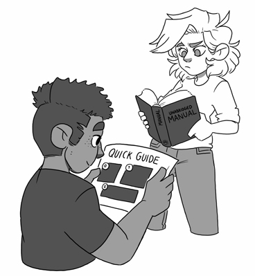

抽象和信息隐藏对于良好的程序设计至关重要。它们让我们能够管理程序中各交互部分的复杂性。前面各章用小示例说明如何推理算法、编写证明。那些示例没有考虑抽象（实际上也不需要）。本章展示如何把类型及该类型上的各种操作收集进一个*模块*。其中一个重点，是如何划清模块客户获准知道的内容与仍保留为私有实现细节的内容之间的界限。本章通过实现队列的模块说明这些组织原则。Abstraction and information hiding are critical to good program design. They allow us to manage the complexity of interacting parts of a program. The chapters so far used small examples to illustrate how to reason about algorithms and how to write proofs. In those examples, there was no concern about (or need for, really) abstraction. In this chapter, I will show how to collect a type and various operations on that type into a *module*. One focus in this endeavor is how to draw the line between what clients of the module are allowed to know and what will remain as private details of the implementation. The chapter illustrates these organizational principles by a module that implements a queue.

## 9.0. 将声明组织进模块9.0. Grouping Declarations into Modules

模块的一个基本作用是将相关声明组织在一起。例如，第6章定义了类型List、列表操作及关于操作的引理。可以把这些声明放进模块，称为ListLibrary。One basic role of a module is to group together related declarations. For example, in Chapter 6, we defined a type List along with operations on lists and lemmas about those operations. We can place these declarations in a module, call it ListLibrary.

**module** ListLibrary {

**datatype** List<T> = Nil | Cons(head: T, tail: List<T>)

**function** Append(xs: List, ys: List): List

// …

**lemma** AppendAssociative(xs: List, ys: List, zs: List)

**ensures** Append(Append(xs, ys), zs) == Append(xs, Append(ys, zs))

// …

// many other declarations go here…

}

模块不仅将相关声明组织起来，还划分程序的*命名空间*。这意味着可在多个模块中引入相同标识符。例如，模块StackLibrary也可声明名为Append的函数（或类型、引理以及其他内容）。要限定所指的是哪个Append，在其前面加上模块名和“.”。例如，从ListLibrary模块外引用ListLibrary模块的Append函数，写作ListLibrary.Append。Not only does a module group together related declarations, but it also divides up the program's *namespace*. This means that the same identifier can be introduced in multiple modules. For example, a module StackLibrary can also declare a function (or type or lemma or whatever) called Append. To qualify which Append you are referring to, you prefix it with the name of the module and a “.”. For example, to refer to the ListLibrary module's Append function from outside the ListLibrary module, you write ListLibrary.Append.

并列放置的两个声明，即同一*作用域*中的声明，称为*同级声明*。假设方法Main与模块ListLibrary同级，那么方法可以使用名称ListLibrary。而且更有意思的是，方法可以通过在限定名称中提及ListLibrary来引用ListLibrary的声明。以下示例说明这一点：Two declarations placed alongside each other—that is, in the same *scope*—are known as *siblings*. Suppose there is a method Main that is a sibling of the module ListLibrary. The method can then use the name ListLibrary. Furthermore (and more interestingly), the method can refer to ListLibrary declarations by mentioning ListLibrary in qualified names. The following example illustrates:

**method** Main() {

**var** xs, i := ListLibrary.Nil, 0;

**while** i < 5 {

xs, i := ListLibrary.Cons(i, xs), i + 1;

}

**print** xs, "\n";

}

## 9.1. 模块导入9.1. Module Imports

模块不能随意引用其他模块。更确切地说，同级模块的名称不会自动包含在其他模块中。例如，以下程序不合法：A module cannot refer to another module willy-nilly. More precisely, the names of sibling modules are not automatically included in other modules. For example, the following program is not legal:

**module** ModuleA {

**function** Plus(x: **int**, y: **int**): **int** {

x + y

}

}

**module** ModuleB {

**function** Double(x: **int**): **int** {

ModuleA.Plus(x, x) // error: unresolved identifier ’ModuleA’

}

}

要在同级模块ModuleB内部包含模块名称ModuleA，后者必须*导入*前者。通过ModuleB内部的**import**声明实现：To include the module name ModuleA inside the sibling module ModuleB, the latter must *import* the former. This is achieved by an **import** declaration inside ModuleB:

**module** ModuleB {

**import** ModuleA

**function** Double(x: **int**): **int** {

ModuleA.Plus(x, x)

}

}

更一般地，**import**声明允许导入方模块指定另一个局部名称，以引用被导入模块。例如，在More generally, the **import** declaration gives the importing module the ability to indicate a different local name for referring to the imported module. For example, in

**module** ModuleB {

**import** A = ModuleA

**function** Double(x: **int**): **int** {

A.Plus(x, x)

}

}

中，**import**声明在ModuleB内部引入局部名称A，并将它绑定为模块ModuleA。事实上，更简单的声明**import** ModuleA只是**import** ModuleA = ModuleA的简写。（注意，**import**声明中“=”的右侧很特殊，因为它能够引用不在模块内部作用域中的名称。）the **import** declaration introduces the local name A inside ModuleB and binds this name to the module ModuleA. In fact, the simpler declaration **import** ModuleA is just a shorthand for **import** ModuleA = ModuleA. (Note that the right-hand side of the “=” in the **import** declaration is rather special, because it has the ability to refer to names that are not in scope inside the module.)

程序中的模块导入不得成环。换言之，合法程序的导入关系形成模块层次结构。例如，若ModuleB导入ModuleA，则ModuleA不得导入ModuleB。The module imports in a program are not allowed to be cyclic. In other words, the import relation in a legal program forms a hierarchy of modules. For example, if ModuleB imports ModuleA, then ModuleA is not allowed to import ModuleB.

## 9.2. 导出集9.2. Export Sets

模块不只是划分程序命名空间，还促进*信息隐藏*。这意味着某些声明或声明的某些部分在模块外不可访问。通过隐藏部分声明，模块得以私下决定实现方式。未来版本可自由修改这些私有实现决策，而不影响模块任何客户。Modules do more than divide up the namespace of a program. They facilitate *information hiding*. This means that certain declarations, or certain parts of declarations, are not accessible outside the module. By hiding some portions of its declarations, a module gains the ability to make private implementation decisions. Such private implementation decisions can freely be changed in future versions of the module without disturbing any client of the module.

在Dafny中，模块哪些部分可在模块外使用，由*导出集*控制。它们由**export**声明引入。如果模块不包含任何**export**声明，则模块中的一切都对导入方可用。例如，第9.0节的ListLibrary模块和第9.1节的ModuleA都默认导出一切。In Dafny, which parts of a module are available outside the module is controlled by *export sets*. These are introduced by the **export** declaration. If a module does not include any **export** declaration, then everything in the module becomes available to importers of the module. For example, the ListLibrary module in Section 9.0 and ModuleA in Section 9.1 default to exporting everything.

几乎每个声明都包含某种*签名*和某种*主体*。签名包含声明引入的名称、类型或参数，以及任何规约子句。主体是声明的其余部分，通常是花括号内的表达式或语句，或=后面的某个定义。Most every declaration consists of some kind of *signature* and some kind of *body*. The signature consists of the name introduced by the declaration, its type or parameters, and any specification clauses. The body is the rest of the declaration and typically consists of an expression or statement inside curly braces or some definition that follows an =.

例如，考虑以下两个声明：For example, consider the following two declarations:

**datatype** Color = Blue | Yellow | Green | Red

**function** Double(x: **int**): **nat**

**requires** 0 <= x

**ensures** Double(x) % 2 == 0

{

**if** x == 0 **then** 0 **else** 2 + Double(x - 1)

}

Color的签名只有名称Color，Double的签名则是其类型签名、前置条件与后置条件。Color主体是“=”后的内容，Double主体是花括号中的表达式。The signature of Color is just the name Color and the signature of Double is its type signature, precondition, and postcondition. The body of Color is what follows the “=” and the body of Double is the expression in curly braces.

Dafny的导出机制可以控制：是同时导出声明的签名和主体，还是只导出签名，或两者都不导出。具体来说，**export**声明的**provides**子句列出要导出签名的声明名称，**export**声明的**reveals**子句列出要同时导出签名和主体的声明名称。The export mechanism in Dafny gives control over the decision to export both the signature and body of a declaration, just the signature, or neither. In more detail, the **provides** clause of the **export** declaration lists the names of those declarations whose signature is to be exported and the **reveals** clause of the **export** declaration lists the names of those declarations whose signature and body are to be exported.

为作说明，考虑以下模块：For illustration, consider the following modules:

**module** ModuleC {

**export**

**provides** Color

**reveals** Double

**datatype** Color = Blue | Yellow | Green | Red

**function** Double(x: **int**): **nat**

**requires** 0 <= x

**ensures** Double(x) % 2 == 0

{

**if** x == 0 **then** 0 **else** 2 + Double(x - 1)

}

}

**module** ModuleD {

**import** ModuleC

**method** Test() {

**var** c: ModuleC.Color;

c := ModuleC.Yellow; // error: unresolved identifier ‘Yellow’

**assert** ModuleC.Double(3) == 6;

}

}

ModuleC的导出集提供类型Color的签名，并揭示函数Double的签名和主体。由于ModuleD导入ModuleC，可以在ModuleD中使用类型ModuleC.Color。示例在局部变量c声明中使用此类型。但是，由于ModuleC仅提供Color，而不揭示它，ModuleD不知道Color的构造器，因此ModuleD中的那条赋值语句不允许使用。事实上，ModuleD甚至不知道Color是归纳数据类型，只知道Color是某个类型。另一方面，ModuleC中的导出集揭示Double，因此ModuleD既可引用函数，也可推理其值。特别是，ModuleD中的断言可以验证。The export set of ModuleC provides the signature of the type Color and reveals both the signature and body of the function Double. Since ModuleD imports ModuleC, the type ModuleC.Color can be used in ModuleD. The example uses this type in the declaration of local variable c. However, since Color is only provided by ModuleC, not revealed, the constructors of Color are not known in ModuleD, so the particular assignment statement in ModuleD is not allowed. In fact, ModuleD does not even get to know that Color is an inductive datatype—all it can tell is that Color is a type. On the other hand, the export set in ModuleC reveals Double, so ModuleD can both refer to the function and reason about its value. In particular, the assertion in ModuleD can be verified.

导出集必须提供模块的自包含视图：如果删除未导出的内容，余下的程序仍须通过类型检查。首先，提及的所有标识符都必须有可用声明。考虑以下模块来说明：An export set must provide a self-contained view of the module: if you delete what is not exported, then what remains must be a program that still type checks. For one, all identifiers mentioned must have an available declaration. To illustrate, consider the following module:

**module** ModuleE {

**datatype** Parity = Even | Odd

**function** F(x: **int**): Parity

{

**if** x % 2 == 0 **then** Even **else** Odd

}

}

假设模块导出集只提供函数F，声明如下：Suppose the export set of this module were to just provide the function F, which would be declared as follows:

**export provides** F // inconsistent export

// set for ModuleE

这不合法，因为删除未导出内容后，剩下This would be illegal, because after deleting what is not exported, what remains is

**function** F(x: **int**): Parity

其中Parity将是未知类型。换言之，对导入ModuleE的模块而言，F声明看起来是畸形的，因为它提到Parity，而导入方不知道其声明。类似地，导出声明where Parity would be an unknown type. In other words, to a module that imports ModuleE, the declaration of F would seem malformed, because it mentions Parity, whose declaration is not known to the importer. Similarly, an export declaration

**export provides** Parity **reveals** F // inconsistent export

// set for ModuleE

也不合法。此时，导出集使以下内容可用：would not be legal either. Here, what is made available by the export set is:

**type** Parity

**function** F(x: **int**): Parity

{

**if** x % 2 == 0 **then** Even **else** Odd

}

其中Even和Odd将是无法解析的标识符。where Even and Odd would be unresolved identifiers.

ModuleE的一个一致导出集示例是An example of a consistent export set for ModuleE is

**export**

**provides** Parity, F

它使以下声明可用：It makes the following declarations available:

**type** Parity

**function** F(x: **int**): Parity

另一个合法导出集是：Another legal export set is:

**export**

**reveals** Parity, F

它使类型Parity和函数F的一切都对导入方可用。由于它们是模块中仅有的两个声明，导出声明也可写成which makes everything about type Parity and function F available to importers. Since those are the only two declarations in this module, the export declaration can also be given as

**export**

**reveals** *

如前所见，完全没有**export**声明时，这也是默认导出集。which, as we have seen before, is also the default export set if there is no **export** declaration at all.

## 9.3. 队列的模块化规约9.3. Modular Specification of a Queue

尝试把良好的信息隐藏应用于不可变队列实现。*队列*是带有三种操作的元素列表：*初始化*创建空队列，*入队*将元素接在队列尾部，*出队*移除并返回队首元素。这里考虑的队列是*不可变*的，因此每个操作返回队列值，而不修改已有队列。Let's try our hand at applying good information hiding to the implementation of an immutable queue. A *queue* is a list of elements with three operations: *initialization* creates an empty queue, *enqueue* appends an element to the queue, and *dequeue* removes and returns an elements from the head of the queue. The queues we consider here are *immutable*, so each operation returns a queue value rather than modifying some existing queue.

### 9.3.0. 基本队列接口9.3.0. A basic queue interface

描述队列最基本的模块如下：The most basic module describing a queue is the following:

**module** ImmutableQueue {

**type** Queue<A>

**function** Empty(): Queue

**function** Enqueue<A>(q: Queue, a: A): Queue

**function** Dequeue<A>(q: Queue): (A, Queue)

**requires** q != Empty()

}

这还不是完整模块，将逐步构建。这里展示的是模块*客户*（即模块使用者）所见的样子。这样的视图称为模块*接口*，因为它描述模块客户与实现如何相互衔接。This is not yet a complete module—let me build it up one step at a time. What I have shown here is how a *client* of the module (that is, a user of the module) would see it. Such a view of a module is called the module *interface*, because it describes how the module's clients and implementation interface with one another.

此模块接口声明了以某个元素类型A为参数的类型Queue。除名称和类型参数个数外，模块未揭示该类型的任何信息。这是良好的信息隐藏实践，因为它使实现可以自由决定如何表示类型值。我们说，它对实现作了*抽象*，也就是可以用更高层、更抽象的术语讨论队列。This module interface declares a type Queue, parameterized by some element type A. The module does not reveal anything about this type other than its name and number of type parameters. This is good information-hiding practice, because it gives the implementation freedom in how to represent values of the type. We say it *abstracts* over the implementation, which simply means that we can speak of queues in higher-level, more abstract terms.

三种操作声明为函数。由于出队操作不能应用于空队列，它有前置条件。The three operations are declared as functions. Since the dequeue operation cannot be applied to an empty queue, it has a precondition.

### 9.3.1. 抽象函数9.3.1. Abstraction functions

上面的基本队列接口过于简单，没有向客户提供足够信息来验证队列的使用。例如，客户无法从基本接口判断Enqueue操作是否可能返回空队列，这使得调用Dequeue很困难。为更详细地描述操作，如果能够谈论队列究竟是什么，就会很有帮助。The basic queue interface above is too simple, because it does not give a client enough information to verify its use of the queue. For example, a client cannot tell from the basic interface whether or not the Enqueue operation may return an empty queue, which makes ever calling Dequeue diﬃcult. To describe the operations in more detail, it would be helpful to be able to speak about what a queue really is.

队列由元素列表组成。如果可以谈论这个列表，规约就能有用且易懂。就是这么简单！引入从队列到其元素列表的函数：A queue consists of a list of elements. If we could speak about that list, it would make for useful and intelligible specifications. It's that easy! Let's introduce a function from a queue to its list of elements:

**ghost function** Elements(q: Queue): List

函数声明为幽灵函数，因为只打算在规约中使用它。队列可能实现为列表，但拥有此函数并不限制队列实现必须是列表。我们说此函数对实现作了*抽象*，并称其为*抽象函数*，因为它让我们能在高于最终实现的层次思考队列。The function is declared as ghost, because we intend to use this function only in specifications. It could be that the queue is implemented as a list, but just because we have this function does not constrain our implementation of the queue to be a list. We say that this function *abstracts* over the implementation and that the function is called an *abstraction function*, because it lets us think of the queue at a level that is higher than its eventual implementation.

无论设计什么模块，都应思考模块提供什么抽象。这样，当深入实现细节时，就能保持思路清晰。Whatever module you are designing, it is a good idea to think about what abstraction the module provides. Doing so gives you clarity of mind when you dip into the implementation details.

用抽象函数Elements，可以用元素列表来规约队列操作。规约既可以以内在方式给出（在函数后置条件中），也可以以外在方式给出（在独立引理中）。这里采用外在方式。修改后的模块接口如下：Using the abstraction function Elements, we can specify the queue operations in terms of lists of elements. The specifications can be given intrinsically (in the postcondition of the functions) or extrinsically (in separate lemmas). Let us do it extrinsically. Here is our revised module interface:

**module** ImmutableQueue {

**import** LL = ListLibrary

**type** Queue<A>

**function** Empty(): Queue

**function** Enqueue<A>(q: Queue, a: A): Queue

**function** Dequeue<A>(q: Queue): (A, Queue)

**requires** q != Empty()

**ghost function** Elements(q: Queue): LL.List

**lemma** EmptyCorrect<A>()

**ensures** Elements(Empty<A>()) == LL.Nil

**lemma** EnqueueCorrect<A>(q: Queue, x: A)

**ensures** Elements(Enqueue(q, x)) == LL.Snoc(Elements(q), x)

**lemma** DequeueCorrect(q: Queue)

**requires** q != Empty()

**ensures var** (a, q’) := Dequeue(q);

LL.Cons(a, Elements(q’)) == Elements(q)

}

为谈论列表，模块导入ListLibrary模块。将多次引用ListLibrary中的声明，因此使用较短名称限定会更方便。为此，**import**声明引入局部名称LL来代表导入的库。In order for the module to talk about lists, it imports the module ListLibrary. We are going to refer to the declarations in ListLibrary many times, so it will be convenient to have a shorter name to use in qualifications. For this reason, the **import** declaration introduces the local name LL to stand for the imported library.

模块ImmutableQueue引用模块ListLibrary内部声明时，在前面加“LL.”。例如，在模块ListLibrary内部，数据类型构造器Cons可仅称为Cons（因为该名称不与ListLibrary中其他声明冲突），也可称为List.Cons，甚至对任意类型B称为List<B>.Cons。因此，从ImmutableQueue引用此构造器，可以写LL.Cons、LL.List.Cons或LL.List<B>.Cons。For module ImmutableQueue to refer to declarations inside module ListLibrary, it prefixes them with “LL.”. For example, inside module ListLibrary, the datatype constructor Cons can be referred to as just Cons (since the name does not clash with other declarations in ListLibrary) or as List.Cons or even List<B>.Cons for any type B. To refer to this constructor from ImmutableQueue, we can therefore write LL.Cons, LL.List.Cons, or LL.List<B>.Cons.

选择把Elements声明为幽灵函数，因为只在规约中使用它。抽象函数通常如此。但如果函数体可编译，且希望运行时也可使用，只需从函数声明中删除关键字**ghost**。I chose to declare Elements as a ghost function, because we will use it only in specifications. This is common for abstraction functions. But if the function's body is compilable and you want to make it available at run time, just remove the keyword **ghost** from the function's declaration.

## 习题9.0。Exercise 9.0.

函数Elements提供队列实现的抽象。另一种更粗粒度的抽象，可以改为引入函数Function Elements provides an abstraction of the queue implementation. Another, more coarse-grained, abstraction would have been to instead introduce a function

**ghost function** Length(q: Queue): **nat**

返回队列的元素个数。编写使用Length而非Elements的模块接口。that returns the number of elements in the queue. Write a module interface that uses Length instead of Elements.

### 9.3.2. 声明导出集9.3.2. Declaring an export set

正在开发的模块尚未显式声明导出集，因此Dafny默认揭示一切。对于目前没有主体的声明，这没问题。但随着完成模块，充分定义类型、函数和引理，就不希望揭示这些定义。显式编写导出集，就能控制客户看到的模块视图。We did not yet explicitly declare an export set in our module-under-development. By default, Dafny will therefore reveal everything. This would be fine for the body-less declarations we have written so far. But as we complete the module to fully define the type, functions, and lemmas, we do not want to reveal those definitions. By writing an export set explicitly, we get to control the clients’ view of the module.

用**export**声明中的**provides**子句列出希望在模块外可用的声明名称。为使导出集自包含，还必须确保向客户提供ListLibrary。通过在导出声明中列出它的局部名称LL实现。We use **provides** clauses in an **export** declaration to list the names of declarations we wish to make available outside the module. To make the export set self-contained, we must make sure to provide clients with the ListLibrary as well. We accomplish this by listing its local name, LL, in the export declaration.

向模块添加以下导出声明：Here is the export declaration we add to the module:

**export**

**provides** Queue, Empty, Enqueue, Dequeue

**provides** LL, Elements

**provides** EmptyCorrect, EnqueueCorrect, DequeueCorrect

由于这些是目前模块声明的所有名称，本可以写成Since these are all the names declared in our module so far, we could have written

**export provides** *

但是，这也会提供以后可能引入的其他辅助函数和引理。However, this would also provide other helper functions and lemmas that we might introduce later.

关于导出已导入模块ListLibrary，再说明一点。若客户模块以名称IQ导入ImmutableQueue，则通过导出名称LL，对于任意类型B，可将列表类型引用为IQ.LL.List<B>。客户也可自行声明导入ListLibrary模块，例如One more remark about exporting the imported module ListLibrary. Through the exported name LL, a client module that imports ImmutableQueue under the name IQ can refer to the list type as IQ.LL.List<B> for any type B. A client can also declare its own import of the ListLibrary module, say

**import** MyOwnLLImport = ListLibrary

然后把IQ.LL.List<B>和MyOwnLLImport.List<B>当作同义名称使用。and then use IQ.LL.List<B> and MyOwnLLImport.List<B> synonymously.

### 9.3.3. 客户示例9.3.3. A sample client

现在有了模块接口，测试一下，确保简单客户能使用它。客户创建空队列，将元素入队，再使该元素出队：Now that we have a module interface, let us test it to make sure it can be used by a simple client. Our client will create an empty queue, enqueue an element, and then dequeue that element:

**module** QueueClient {

**import** IQ = ImmutableQueue

**method** Client() {

**var** q := IQ.Empty();

q := IQ.Enqueue(q, 20);

**var** (a, q’) := IQ.Dequeue(q); // precondition violation

}

}

验证器抱怨Dequeue调用可能违反前置条件。此前已预料到，因此引入了引理。现在使用引理，每个函数调用配一个（呼！），并在最后添加几个断言，检查是否得到预期最终结果：The verifier complains that the call to Dequeue may violate its precondition. We had anticipated this before, which is why we introduced the lemmas. Let us make use of the lemmas—one for each function call (phew!)—and let us also add a couple of assertions at the end to check that we are getting the end results we'd expect:

**module** QueueClient {

**import** IQ = ImmutableQueue

**method** Client() {

IQ.EmptyCorrect<**int**>(); **var** q := IQ.Empty();

IQ.EnqueueCorrect(q, 20); q := IQ.Enqueue(q, 20);

IQ.DequeueCorrect(q); **var** (a, q’) := IQ.Dequeue(q);

**assert** a == 20;

**assert** q’ == IQ.Empty(); // assertion cannot be verified

}

}

现在Dequeue的前置条件可验证，说明引理有用。但它们未完成所有期望的工作，因为验证器抱怨最后一个断言。The precondition of Dequeue can now be verified, so we can see that our lemmas are useful. But they don't do everything we would like, because the verifier complains about the last assertion.

为排查问题，可尝试在失败断言前加入以下断言：To debug this situation, we can try to precede the failing assertion with the following assertion:

**assert** IQ.Elements(q’) == IQ.LL.Nil;

此断言通过验证了！既然知道q’表示空元素列表，为什么不能验证它等于IQ.Empty()？后者（由EmptyCorrect()可知）也表示空元素列表。This assertion goes through the verifier! So, if we know that q’ represents the empty list of elements, then how come we cannot verify that it equals IQ.Empty(), which (as EmptyCorrect() tells us) also represents the empty list of elements?

问题在于，类型Queue<**int**>可能有多个值表示空元素列表。确实，取决于ImmutableQueue实现采用的数据结构，可能有许多Queue<**int**>值表示同一个元素列表。一般而言，确保类型的所有值都是规范的，即每个值表示不同的抽象值，计算代价可能非常高。The problem is that there may be several values of the type Queue<**int**> that represent the empty list of elements. Indeed, depending on what data structure the implementation of ImmutableQueue uses, there may be many Queue<**int**> values that represent the same list of elements. In general, it can be computationally very expensive to make sure that all values of a type are canonical, that is, that each one represents a different abstract value.

现在需要作出决策。一个极端是，决定客户绝不直接比较Queue值，而总是借助抽象函数Elements比较。另一个极端是，决定实现必须支持直接比较Queue值，实质上就是确保函数Elements为*单射*（即Elements是一一对应到其像的函数）。这里采用两个极端之间的良好折中：让Elements对于空队列是单射。换言之，使Empty()成为Queue中唯一表示空元素列表的值。通过在ImmutableQueue中添加另一个引理实现：We have a decision to make. At one extreme, we can decide that a client should never compare a Queue value directly, but should always resort to comparisons via the abstraction function Elements. At the other extreme, we can decide that the implementation must make it possible to compare Queue values directly, which essentially comes down to making sure function Elements is *injective* (that is, that Elements is a one-to-one function). We will settle for a good choice in between these two extremes, namely to make Elements injective for the empty queue. Stated differently, we will make Empty() the only value of Queue that represents the empty list of elements. We accomplish this by adding another lemma in ImmutableQueue:

**lemma** EmptyUnique(q: Queue)

**ensures** Elements(q) == LL.Nil ==> q == Empty()

并且（别忘记！）在模块导出子句的**provides**子句中添加EmptyUnique。与通常一样，此引理性质有多种表达方式（参见第7.1节对LessTransitive的讨论）。这里选择在后置条件中使用蕴含，而不把前件写成前置条件。这样可以使用引理的逆否形式，即用已知不等于Empty()的q调用引理，调用者便可得出Elements(q) != LL.Nil。and (don't forget!) adding EmptyUnique to the **provides** clause of the module's export clause. As usual, there are several ways to express the property of this lemma (see the discussion of LessTransitive in Section 7.1). Here, I chose to use an implication in the postcondition, rather than writing the antecedent in a precondition. This makes it possible to use the contrapositive of the lemma. That is, by calling the lemma with a q that is known not to be Empty(), a caller is able to conclude Elements(q) != LL.Nil.

最后，简单客户终于可以验证：Finally, our simple client can be verified:

**module** QueueClient {

**import** IQ = ImmutableQueue

**method** Client() {

IQ.EmptyCorrect<**int**>(); **var** q := IQ.Empty();

IQ.EnqueueCorrect(q, 20); q := IQ.Enqueue(q, 20);

IQ.DequeueCorrect(q); **var** (a, q’) := IQ.Dequeue(q);

**assert** a == 20;

IQ.EmptyUnique(q’);

**assert** q’ == IQ.Empty();

}

}

虽然完成任务，但看起来确实杂乱。第10.3节将着手减少这种杂乱。接下来准备实现ImmutableQueue。This gets the job done, but it sure looks cluttered. We'll work on reducing clutter like this in Section 10.3. Next, we are ready to take on the implementation of ImmutableQueue.

## 习题9.1。Exercise 9.1.

编写客户模块（如QueueClient），测试习题9.0的模块接口。调整队列接口，使客户模块通过验证。Write a client module (like QueueClient) to test the module interface in Exercise 9.0. Adjust the queue interface so that your client module verifies.

### 9.3.4. 队列实现9.3.4. Queue implementation

回到模块ImmutableQueue。要完成它，需要定义类型Queue、四个函数以及四个引理。We return to module ImmutableQueue. To make it complete, we need to define the type Queue, the four functions, and the four lemmas.

队列的一种简单实现是使用列表，即Elements返回的同一个列表。但Enqueue操作需要将元素接在列表末尾，其代价与队列长度成正比。获得更好实现的关键思路是使用两个列表，称为front和rear。队首的一部分元素存储在front中，可在常数时间内出队。其余元素以*逆序*存储在rear中，使入队能在常数时间内完成。当Dequeue操作发现front为空时，把rear元素复制*并反转*到front中。因此，每个出队元素都经历两次常数时间操作，并参与一次反转。如第6.6节所见，列表反转需要线性时间，因此Dequeue的*摊还*运行时间为常数。这意味着，随着队列演变，创建该队列的Dequeue操作总运行时间，是Dequeue调用次数的常数倍。One simple implementation for our queue would be to use a list, the same list that Elements returns. However, the cost of appending an element to the list, as the Enqueue operation would do, is proportional to the length of the queue. The key idea behind getting a better implementation is to use two lists, call them front and rear. A portion of the elements at the head of the queue are stored in front, where they can be dequeued in constant time. The rest of the elements are stored in rear in *reverse order*, which lets them be enqueued in constant time. When the Dequeue operation finds front empty, it copies *and reverses* the elements from rear into front. Consequently, each element dequeued will have undergone two constant-time operations and been part of one reversal. As we have seen in Section 6.6, list reversal requires linear time, so Dequeue will have an *amortized* running time that is constant. This means that as a queue evolves, the sum of the running times of Dequeue operations that created the queue is a constant multiple of the number of Dequeue invocations.

实现首先定义数据结构类型。将声明**type** Queue<A>替换为以下内容：We start our implementation by defining the type of the data structure. We replace the declaration **type** Queue<A> with the following:

**datatype** Queue<A> = FQ(front: LL.List<A>, rear: LL.List<A>)

注意，由于模块仅*提供*而不*揭示*类型Queue，Queue被定义为数据类型这一事实仍是模块私有实现决策。Note, since our module only *provides*, not *reveals*, the type Queue, the fact that Queue is defined as a datatype remains a private implementation decision in the module.

此队列实现的关键思路由Elements定义刻画：The key idea of this queue implementation is captured in the definition of Elements:

**ghost function** Elements(q: Queue): LL.List {

LL.Append(q.front, LL.Reverse(q.rear))

}

其他函数也容易编写：The other functions are also easy to write:

**function** Empty(): Queue {

FQ(LL.Nil, LL.Nil)

}

**function** Enqueue<A>(q: Queue, x: A): Queue {

FQ(q.front, LL.Cons(x, q.rear))

}

**function** Dequeue<A>(q: Queue): (A, Queue)

**requires** q != Empty()

{

**match** q.front

**case** Cons(x, front’) =>

(x, FQ(front’, q.rear))

**case** Nil =>

**var** front := LL.Reverse(q.rear);

(front.head, FQ(front.tail, LL.Nil))

}

引理EmptyCorrect和EmptyUnique会自动完成，只需提供空主体{}，因此不在此展示。其余两个引理的证明很适合作为练习，因此也不在此展示。Lemmas EmptyCorrect and EmptyUnique are done automatically—you need only supply the empty body, {}, so I won't show them here. The proofs of the other two lemmas make for good exercises, so I won't show them here, either.

## 习题9.2。Exercise 9.2.

编写EnqueueCorrect的证明。Write the proof for EnqueueCorrect.

## 习题9.3。Exercise 9.3.

编写DequeueCorrect的证明。Write the proof for DequeueCorrect.

## 习题9.4。Exercise 9.4.

(a) 编写模块BlockChain，声明类型Ledger，带有类型签名如下的三种操作：(a) Write a module BlockChain declaring a type Ledger with three operations that have the following type signatures:

**function** Init(): Ledger

**function** Deposit(ledger: Ledger, n: **nat**): Ledger

**function** Withdraw(ledger: Ledger, n: **nat**): Ledger

编写抽象函数Write an abstraction function

**ghost function** Balance(ledger: Ledger): **int**

报告账本余额，并使n <= Balance(ledger)成为Withdraw的前置条件。声明模块导出集。that reports the balance of a ledger, and make n <= Balance(ledger) be a precondition of Withdraw. Declare an export set for the module.

(b) 用Balance编写各函数的内在规约。编写简单客户，测试行为是否符合预期。(b) Write intrinsic specifications for the functions in terms of Balance. Write a simple client to test that they behave as you'd expect.

(c) 用整数列表实现模块。具体地，将Ledger定义为类型同义词：(c) Implement the module with a list of integers. Specifically, define Ledger to be a type synonym:

**type** Ledger = List<**int**>

其中List是惯用的列表类型。Deposit和Withdraw的实现分别将非负数或非正数添加到列表开头。where List is our usual list type. The implementations of Deposit and Withdraw prepend (a non-negative or non-positive number, respectively) to the list.

（注意，Deposit和Withdraw的参数n是**nat**，而Balance返回**int**。为将Balance声明为返回**nat**，需要数据结构不变式，第10章将介绍，参见习题10.5。）(Note that parameter n to Deposit and Withdraw is **nat**, whereas Balance returns an **int**. In order to declare Balance to return a **nat**, we need a data-structure invariant, which I will cover in Chapter 10, see Exercise 10.5.)

## 9.4. 支持相等运算的类型9.4. Equality-Supporting Types

不可变队列的客户还可能需要一种操作，因此也需要导出：相等运算。如果对此不太关心，可以跳过本节，因为将深入介绍Dafny语言的一些细枝末节。There is one more operation that clients of our immutable queue may want to use and that we thus need to export: equality. If you don't feel too concerned about this, you may want to skip this section, because it goes into a number of picky details of the Dafny language.

### 9.4.0. 相等运算9.4.0. Equality

在Dafny中，每种类型都有内置相等运算符，写作==。例如，整数（**int**）相等就是预期的算术相等，整数集合（**set**<**int**>）相等是数学集合相等，其中元素用整数相等比较。在Dafny幽灵上下文中始终可使用相等运算，但编译上下文中不一定可以。这是因为某些类型值的相等比较可能无法在有限时间内计算，甚至根本不可计算。例如，比较可能无限的整数集合（**iset**<**int**>）需要无限次成员测试，比较整数上的函数（**int** -> **int**）需要在无限多个值上调用函数。In Dafny, every type has a built-in equality operator, written ==. For example, equality on integers (**int**) is the expected arithmetic equality, and equality on sets of integers (**set**<**int**>) is mathematical set equality where the elements are compared using equality on integers. Equality can always be used in ghost contexts in Dafny, but equality cannot always be used in compiled contexts. This is because the values of some types may not be computable in finite time or at all. For example, to compare possibly infinite sets of integers (**iset**<**int**>) requires an infinite number of membership tests, and to compare functions on integers (**int** -> **int**) requires invoking the function on an infinite number of values.

因此，Dafny会跟踪哪些类型已知具有*可编译*相等运算，称为“支持相等运算的类型”。此名称略欠准确，因为所有类型在幽灵上下文中都支持相等运算。当类型定义可用时，Dafny用定义判断类型是否支持相等运算。但对于类型参数、不透明类型，或导出集仅*提供*的类型，无法这样判断。这时，可以显式声明该类型指的是支持相等运算的类型。做法是在类型声明的名称后写*类型特征*（==）。（第6.5节的函数Find中已经见过一个实例。）For this reason, Dafny keeps track of which types are known to have a *compilable* equality operation. These are referred to as “equality-supporting types”—a slight misnomer, since all types support equality in ghost contexts. When the definition of a type is available, Dafny uses the definition to figure out whether or not the type supports equality. This is not possible for type parameters, opaque types, or types that are just *provided* by an export set. In such cases, we can explicitly declare that the type refers to an equality-supporting type. This is done by writing the *type characteristic* (==) after the name of the type in its declaration. (We saw an instance of this already, for function Find in Section 6.5.)

考虑模块ImmutableQueue的客户，它定义Dequeue的变体，可用于任意队列，在给定空队列时返回默认值。这样的客户模块如下：Consider a client of module ImmutableQueue that defines a variation of Dequeue, one that can be applied to any queue and that returns a default value when given an empty queue. Here is such a client module:

**module** QueueExtender {

**import** IQ = ImmutableQueue

**function** TryDequeue<A>(q: IQ.Queue, default: A): (A, IQ.Queue)

{

**if** q == IQ.Empty() **then** (default, q) **else** IQ.Dequeue(q)

}

}

采用之前定义的ImmutableQueue时，Dafny抱怨函数TryDequeue试图用==比较类型IQ.Queue<A>的值。在模块QueueExtender中，并不知道IQ.Queue<A>是否支持相等运算。下面考虑脱离这一困境的两种可能方法。With ImmutableQueue as we defined it, Dafny complains that function TryDequeue uses == to try to compare values of type IQ.Queue<A>. In module QueueExtender, it is not known whether or not IQ.Queue<A> supports equality. We will consider two possible ways out of this quagmire.

### 9.4.1. 明确声明相等运算支持9.4.1. Explicating equality support

一种出路是，从模块ImmutableQueue导出类型Queue<A>确实支持相等运算这一事实。你可能以为，只需在**datatype**声明中添加(==)：One way out of the quagmire is to export, from module ImmutableQueue, that type Queue<A> does indeed support equality. You might think this would be done by adding a (==) in the **datatype** declaration:

**datatype** Queue(==)<A> = // syntax error

FQ(front: LL.List<A>, rear: LL.List<A>)

但是，(==)标记除可用于类型参数（如第6.5节的Find）外，只能用于**type**声明。这没问题，只需重命名数据类型，再用**type**声明定义要导出的*类型同义词*：However, the (==) mark can be used (for type parameters, as we saw for Find in Section 6.5 or) only in **type** declarations. That's not a problem—we simply rename the datatype and use a **type** declaration to define a *type synonym* that we export:

**type** Queue(==)<A> = // claimed equality support is in error Queue’<A>

**datatype** Queue’<A> = FQ(front: LL.List<A>, rear: LL.List<A>)

这几乎可行。问题在于，数据类型Queue’<A>并非总支持相等运算！只有类型参数A支持时，它才支持。因此，要声称Queue<A>支持相等运算，就必须把定义限制为支持相等运算的A。做法是也给类型参数添加(==)标记：This almost works. The problem is that the datatype Queue’<A> does not always support equality! It supports equality only if the type parameter A does. So, to claim that Queue<A> supports equality, we must restrict the definition to A's that support equality. This is done by marking the type parameter with (==) as well:

**type** Queue(==)<A(==)> = Queue’<A>

**datatype** Queue’<A> = FQ(front: LL.List<A>, rear: LL.List<A>)

## 习题9.5。Exercise 9.5.

为什么在第9.3.3节的方法Client()中比较q’ == IQ.Empty()时，还不需要(==)？How come we didn't need (==) already when we compared q’ == IQ.Empty() in method Client() in Section 9.3.3?

### 9.4.2. 导出判空谓词9.4.2. Exporting an emptiness predicate

另一种出路是，ImmutableQueue不导出队列==操作本身，而只导出将队列与Empty()比较的测试。毕竟，如第9.3.3节说明引入EmptyUnique引理的动机时所述，Queue值上的相等运算不太有用，因为多个Queue值表示同一个元素列表。但相等运算对空队列*确实*有用，因为ImmutableQueue为空队列使用唯一表示。实际上，还可以说，早在第9.3.0节使用前置条件q != Empty()就是错误，因为它已经假定空队列具有唯一表示。Another way out of the quagmire is for ImmutableQueue to export not the queue == operation itself but only a test that compares a queue with Empty(). After all, as I remarked in Section 9.3.3 where I motivated the introduction of the EmptyUnique lemma, equality on Queue values is not so useful, because there are several Queue values that represent the same list of elements. But equality *is* useful for the empty queue, because ImmutableQueue is using a unique representation for the empty queue. Actually, you could also argue that using the precondition q != Empty()—back in Section 9.3.0—was a mistake, because it already assumes a unique representation for the empty queue.

采取这种摆脱困境的策略时，保持先前Queue的**datatype**声明不变，并在模块ImmutableQueue中添加以下编译谓词：Under this quagmire exit strategy, we keep the **datatype** declaration of Queue as we had it before, and we add to module ImmutableQueue the following compiled predicate:

**predicate** IsEmpty(q: Queue)

**ensures** IsEmpty(q) <==> q == Empty()

{

q == FQ(LL.Nil, LL.Nil)

}

还在ImmutableQueue的**export**声明的**provides**子句中添加IsEmpty。We also add IsEmpty in a **provides** clause of the **export** declaration in ImmutableQueue.

查看IsEmpty主体，可能会疑惑为何能用相等运算比较q：q所属类型只有在q元素类型支持相等运算时才支持它。解释是，作为特例，Dafny允许与仅由字面量组成的表达式比较，例如FQ(LL.Nil, LL.Nil)。毕竟，这种比较也可用**match**表达式或数据类型判别器FQ?和Nil?完成。（提醒一下，后置条件中的比较q == Empty()也允许，因为Dafny在幽灵上下文中始终支持相等运算。）Looking at the body of IsEmpty, you may wonder how it can compare q using equality, since q is of a type that supports equality only if the element type of q supports equality. The explanation is that, as a special case, Dafny allows comparisons with expressions that consist of just literals, like FQ(LL.Nil, LL.Nil). After all, such a comparison could also be done with **match** expressions or with the datatype discriminators FQ? and Nil?. (As a reminder, the comparison q == Empty() in the postcondition is also allowed, because Dafny always supports equality in ghost contexts.)

## 习题9.6。Exercise 9.6.

不使用(==)，改写模块QueueExtender，使其使用IsEmpty。Without using (==), rewrite module QueueExtender to use IsEmpty.

## 习题9.7。Exercise 9.7.

导出模块ImmutableQueue的两个新成员：返回给定队列元素个数的编译函数Length，以及关于Length(q)的正确性引理，说明它返回列表Elements(q)的长度。由此可知，测试Length(q) == 0与q == Empty()结果相同。改写模块QueueExtender中的函数TryDequeue，使其使用Length。Export two new members of module ImmutableQueue: a compiled function Length that returns the number of elements in a given queue, and a correctness lemma about Length(q) that says it returns the length of the list Elements(q). From these, it follows that the test Length(q) == 0 gives the same result as would q == Empty(). Rewrite function TryDequeue in module QueueExtender to use Length.

## 习题9.8。Exercise 9.8.

习题9.7建议的TryDequeue实现不太高效。为什么？The implementation of TryDequeue as suggested in Exercise 9.7 is not very eﬃcient. Why?

## 9.5. 小结9.5. Summary

模块化设计在软件工程中至关重要。它引导程序分解，使实现决策可以隐藏在模块内部。David Parnas指出了这一点，可概括为口号“每个模块都有一个秘密”[108]。为在这种信息隐藏存在时仍能编写规约和进行验证，需要对细节作抽象。本章展示了如何用抽象函数（示例中的Elements）实现：将正在实现的值映射为其他已知、更简单类型的值。Modular design is crucial in software engineering. It leads to a program decomposition where implementation decisions can be hidden inside modules. David Parnas pointed this out, in what can be summarized in the slogan “every module has one secret” [108]. To make it possible to write specifications and do verification in the presence of such information hiding, we abstract over the details. In this chapter, I showed how that can be done using an abstraction function (Elements, in the example) that maps the values we are implementing to values of other, known, simpler types.

声明划分到各个模块中，模块导入其依赖的模块。通过声明导出集，模块决定哪些声明对客户可用。对于导出集中的每个声明，可以选择仅包含声明签名（用**provides**子句），或同时包含签名与主体（用**reveals**子句）。Declarations are divided up into modules, and a module imports the modules it relies on. By declaring an export set, a module decides which declarations are to be available to clients. For each declaration in an export set, the export set can choose to include just the signature of the declaration (using **provides** clauses) or both the signature and body of the declaration (using **reveals** clauses).

## 注释Notes

Chris Okasaki的《*纯函数式数据结构*》（Purely Functional Data Structures）[104]介绍了许多有趣而有用的函数式数据结构实现，例如第9.3.4节的队列实现。Many fun and useful implementations of functional data structures, such as the queue implementation in Section 9.3.4, are found in Chris Okasaki's book on *Purely Functional Data Structures* [104].

为支持信息隐藏，编程语言提供*访问控制*机制，限制声明可见性。如前所见，Dafny模块中声明的访问控制通过导出集定义。许多基于类的面向对象语言，包括Java和C#，允许用访问修饰符声明**class**成员，如**private**（仅在类实现中可见）和**public**（在能访问类的任何上下文中可用）。C++和Eiffel还允许一个类的成员声明“友元”类，给予成员访问特权。其他语言，包括SPARK [117]、Oberon-2和Go，在模块层次使用私有/公开机制。To support information hiding, programming languages provide mechanisms of *access control* that limit the visibility of declarations. As we have seen, access control for the declarations in a module in Dafny is defined via export sets. Many class-based object-oriented languages, including Java and C#, allow members of a **class** to be declared with access modifiers like **private** (meaning, visible only in the implementation of the class) and **public** (meaning, usable in any context that has access to the class). C++ and Eiffel additionally allow members of one class to declare “friend” classes that get privileged access to the members. Other languages, including SPARK [117], Oberon-2, and Go, use a private/public mechanism at the module level.

许多编程语言的访问控制机制只管理客户是否能访问给定声明。这对于编译已足够。但涉及规约和证明时，还需要限制声明的*含义*有多少对客户可见。因此，Dafny提供两个声明导出层次（**provides**和**reveals**）[80]，F* [53]则允许模块接口包含语义信息。In many programming languages, access-control mechanisms govern only whether or not a client has access to a given declaration. This is suﬃcient for compilation. But when specifications and proofs are involved, it is also important to be able to restrict how much of the *meaning* of a declaration is visible to a client. For this reason, Dafny offers two levels of exporting declarations (**provides** and **reveals**) [80], and F* [53] allows its module interfaces to contain semantic information.

本书每个模块只有一个导出集，这是常见情况。其他情况下，模块可能需要向不同客户呈现不同视图。例如，模块可能想向某个“友元”模块揭示其表示的某些细节。为此，Dafny允许模块声明多个导出集[80]。Modula-3的模块和接口也提供这种灵活性[100]。Each module in this book has only one export set, which is the common case. In other cases, a module may need to present different clients with different views of the module. For example, a module may want to reveal some detail of its representation to some “friend” module. For this purpose, Dafny allows a module to declare several export sets [80]. This kind of flexibility is also provided by the modules and interfaces in Modula-3 [100].

抽象可通过多种方式实现。本章使用抽象函数，即讨论某些值但不把实现限制为这些值的任何特定表示的幽灵函数。抽象函数在验证工具中很常见。第16和17章将通过幽灵字段结合有效性谓词实现抽象。SPARK语言[117]专门支持声明抽象状态（Abstract_State）及其具体对应状态（Refined_State）。有许多优秀著作教授数据抽象技术；想向真正的抽象大师学习，可以看看使用规约语句的Morgan [93]、使用Event-B的Abrial [0]以及使用TLA<sup>+</sup>的Lamport [73]。Abstraction can be achieved in various ways. In this chapter, we used abstraction functions—ghost functions that speak of some values without constraining the implementation to any particular representation of those values. Abstraction functions are common in verification tools. In Chapters 16 and 17, we'll achieve abstraction by using ghost fields in combination with a validity predicate. The SPARK language [117] has special support for declaring abstract state (Abstract_State) and the concrete counterpart (Refined_State). There are many great texts that teach techniques for abstracting over data; to learn from true masters of abstractions, scope out Morgan using specification statements [93], Abrial using Event-B [0], and Lamport using TLA<sup>+</sup> [73].

# 第10章 数据结构不变式Chapter 10 Data-Structure Invariants

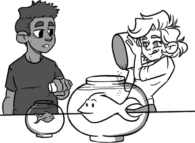

幸好有类型！它们让我们能够描述数据结构的骨架，也给程序分析提供简单方法，检查程序是否保持该骨架。因此，例如可以依赖第4.5节定义的Tree类型值要么是Leaf、要么是Node这一事实。Thank goodness for types! They let us describe the skeleton of a data structure and they give a simple way for a program analysis to check that a program maintains that skeleton. This means we can rely on, for example, the fact that a value of the type Tree defined in Section 4.5 is either a Leaf or a Node.

对于大多数数据结构，设计不只有骨架。每个数据结构值都符合骨架，但并非每个符合骨架的值都可能由数据结构操作产生。例如，*二叉搜索树*以树为骨架，其载荷值按有序方式排列。超出骨架的这类约束称为*数据结构不变式*。不变式对于良好的程序设计与程序正确性至关重要。For most data structures, there is more to the design than just the skeleton. Every value of the data structure matches the skeleton, but not every value that matches the skeleton is a value that the data-structure operations can ever produce. For example, a *binary search tree* is a data structure whose skeleton is a tree and whose payload values are arranged in sorted order. Constraints like these that go beyond the skeleton are called *data-structure invariants*. Invariants are critical to good program design and program correctness.

为说明数据结构不变式，本章以*优先队列*为贯穿始终的示例。普通队列是以先进先出方式访问的元素集合（如第9.3节所见），优先队列则仅允许访问集合中的一个最小元素。先从规约开始，再进入实现。To illustrate data-structure invariants in this chapter, I will use a *priority queue* as the running example. Whereas an ordinary queue is a collection of elements that are accessed in a first-in first-out fashion (as we saw in Section 9.3), a priority queue gives access only to a minimal element of the collection. We start with the specification and then go into the implementation.

## 10.0. 优先队列规约10.0. Priority-Queue Specification

除创建空优先队列和检查是否为空外，优先队列操作包括插入元素和移除最小元素。考虑存储整数的优先队列，因此“最小”按算术比较定义。规约先声明以下简单（且不完整）的模块：Other than creating and checking for an empty priority queue, the operations on a priority queue are insertion of an element and removal of the minimal element. We will consider priority queues that store integers, so “minimal” is defined in terms of arithmetic comparisons. We start our specification by declaring the following simple (and incomplete) module:

**module** PriorityQueue {

**type** PQueue

**function** Empty(): PQueue

**predicate** IsEmpty(pq: PQueue)

**function** Insert(pq: PQueue, y: **int**): PQueue

**function** RemoveMin(pq: PQueue): (**int**, PQueue)

**requires** !IsEmpty(pq)

}

目前模块与第9.3节普通队列的起点很像。这里一开始就决定，不承诺值有唯一表示，甚至空优先队列也不例外，因此模块引入IsEmpty谓词（如第9.4.2节所述）。So far, the module looks a lot like our starting point for ordinary queues in Section 9.3. Here, I have decided right away that we don't want to commit to a unique representation of values, not even the empty priority queue, and therefore the module introduces an IsEmpty predicate (as described in Section 9.4.2).

### 10.0.0. 抽象10.0.0. Abstraction

为更详细地说明这些函数返回什么，需要对每个PQueue值表示的内容作抽象。与第9.3节一样，引入抽象函数，将PQueue映射到其元素。这里可以选择。一种可能是把元素抽象为有序序列（类型**seq**<**int**>）。这样RemoveMin规约容易写，但Insert规约会复杂。另一种可能（也是这里采用的）是把元素抽象为多重集（类型**multiset**<**int**>）。这使Insert规约简单，但使RemoveMin规约稍微复杂一点。To say more about what is returned by these functions, we need some abstraction of what each PQueue value represents. As in Section 9.3, we introduce for this purpose an abstraction function that maps a PQueue to its elements. Here, we have a choice. One possibility is to abstract the elements into a sorted sequence (of type **seq**<**int**>). This will make it easy to write the specification for RemoveMin, but will complicate the specification of Insert. Another possibility (and this is what we will do) is to abstract the elements into a multiset (of type **multiset**<**int**>). This makes the specification of Insert simple, but complicates (only slightly) the specification of RemoveMin.

在模块中引入这样的（仅用于规约的）抽象函数Elements。利用它，以外在方式把函数规约写成独立引理：We introduce such a (specification-only) abstraction function Elements in our module. Using it, we write specifications for our functions extrinsically, as separate lemmas:

**ghost function** Elements(pq: PQueue): **multiset**<**int**>

**lemma** EmptyCorrect()

**ensures** Elements(Empty()) == **multiset**{}

**lemma** IsEmptyCorrect(pq: PQueue)

**ensures** IsEmpty(pq) <==> Elements(pq) == **multiset**{}

**lemma** InsertCorrect(pq: PQueue, y: **int**)

**ensures** Elements(Insert(pq, y))

== Elements(pq) + **multiset**{y}

**lemma** RemoveMinCorrect(pq: PQueue)

**requires** !IsEmpty(pq)

**ensures var** (y, pq’) := RemoveMin(pq);

IsMin(y, Elements(pq)) &&

Elements(pq’) + **multiset**{y} == Elements(pq)

关于RemoveMin的引理使用谓词IsMin，表示y是多重集Elements(pq)的最小元素。可以递归定义IsMin，但更直接的方式是使用*全称量词*（**forall**，数学文献中写作∀），陈述多重集每个元素的性质。第13章将更详细地说明量词；这里的目的只需大致认可IsMin定义正确。The lemma about RemoveMin uses a predicate IsMin, which says that y is a minimal element in the multiset Elements(pq). It's possible to define IsMin recursively, but a much more straightforward way is to use a *universal quantifier* (**forall**, written ∀ in mathematical texts) that can say something about every elements in the multiset. I will illustrate quantifiers in greater detail in Chapter 13; for our purposes here, we only need a head-nodding understanding of that IsMin is defined correctly.

**ghost predicate** IsMin(y: **int**, s: **multiset**<**int**>) {

y **in** s && **forall** x :: x **in** s ==> y <= x

}

用文字说，IsMin(y, s)表示y是多重集s的元素，且对于s中的每个元素x，元素y都不大于元素x。In words, IsMin(y, s) says that y is an element of the multiset s and that for each element x in s, element y is below element x.

从客户角度看，目前的模块相当不错。Our module so far looks pretty good from the point of view of clients.

## 习题10.0。Exercise 10.0.

在客户模块中编写小型测试驱动程序（参见第9.3.3节的QueueClient）。让它向新建优先队列插入两个元素，再两次使用RemoveMin取出。验证两个元素按正确顺序返回。Write a small test harness in a client module (cf. QueueClient in Section 9.3.3). Make the test harness insert two elements into a newly created priority queue and then use RemoveMin twice to retrieve them. Verify that the two elements are returned in the correct order.

提示：为使验证器确信，需要使用一些引理。当然要调用PriorityQueue声明的引理，还需要帮助验证器推理多重集的引理。特别是，需要在测试驱动程序的中间程序点处，编写关于优先队列元素已知情况的一些内联断言。Hint: To convince the verifier of this, you will need to use some lemmas. Of course, you will need to invoke the lemmas declared in PriorityQueue, but you will also need some lemmas to help the verifier reason about multisets. In particular, you will need to write some inline assertions about what is known about the elements of the priority at intermediate program points in test harness.

### 10.0.1. 导出集10.0.1. Export set

继续开发PriorityQueue模块时，明确哪些内容对客户可见，哪些仍是私有实现细节。为此添加显式**export**声明。模块提供目前声明的一切，唯独IsMin将完全揭示。As we continue the development of the PriorityQueue module, let us be clear about what clients get to see and what remains private implementation details. We do that by adding an explicit **export** declaration. The module provides everything we have declared so far, except for IsMin, which it reveals in full.

**export**

**provides** PQueue, Empty, IsEmpty, Insert, RemoveMin

**provides** Elements

**provides** EmptyCorrect, IsEmptyCorrect

**provides** InsertCorrect, RemoveMinCorrect

**reveals** IsMin

此导出集混合使用第9.2节介绍的**provides**和**reveals**子句。This export set uses a mixture of **provides** and **reveals** clauses, which I introduced in Section 9.2.

## 10.1. 设计数据结构10.1. Designing the Data Structure

堆性质使良好性能成为可能：*只要*树平衡，方法Insert和RemoveMin就各能在𝒪(log *n*)时间内执行，即时间与优先队列大小的对数成正比。如果每棵左子树的大小与相邻右子树大致相同，就称树是*平衡*的。The heap property makes it possible to obtain good performance: methods Insert and RemoveMin can each operate in time 𝒪(log *n*) (that is, in time proportional to the logarithm of the size of the priority queue), *provided* the tree is balanced. A tree is *balanced* if every left subtree has roughly the same size as its neighboring right subtree.

保证二叉堆树平衡的一种优美数据结构是*Braun树*。这就是将要实现的结构。Braun树的核心思路是：节点的左右子树大小相同，或左子树比右子树多一个元素。An elegant data structure that ensures that the binary-heap tree is balanced is a *Braun tree*. This is what we are going to implement. The central idea of a Braun tree is that either the left and right subtrees of a node have the same size or the left subtree has one more element than the right subtree.

因此，共有三个性质：值位于内部节点的骨架性质、堆性质，以及Braun树平衡性质。后两种超出骨架的性质称为*数据结构不变式*。So, we have three properties altogether. There's the skeletal property that places values in interior nodes, there's the heap property, and there's the Braun-tree balance property. We call the latter two properties *data-structure invariants*, since they go beyond the skeletal property.

为确保二叉堆骨架性质，将类型PQueue定义为以下数据类型：To ensure the skeletal property of the binary heap, we define type PQueue to be the following datatype:

**type** PQueue = BraunTree

**datatype** BraunTree =

| Leaf

| Node(x: **int**, left: BraunTree, right: BraunTree)

（Dafny允许在第一个构造器名称前写|，像这里这样把构造器声明在不同行时，外观很好。）为确保Braun树的数据结构不变式，需要一些逻辑表达式。(Dafny allows a | before the first constructor name, which looks nice when you declare the constructors on separate lines, as I did here.) To ensure the data-structure invariant of Braun trees, we need to involve some logical expressions.

### 10.1.0. 有效的树10.1.0. Valid trees

优先队列正确性依赖堆性质。因此，为验证，需要区分具有堆性质的树，以及（原则上）可由构造器Leaf和Node构建的其他树。引入称为Valid的谓词实现。其思路是：树满足Valid，当且仅当它可能由PriorityQueue模块返回。The correctness of our priority queue relies on the heap property. Thus, for verification, we need to distinguish those trees that have the heap property from other trees that (in principle) could be built from the constructors Leaf and Node. We do this by introducing a predicate that we shall call Valid. The idea is that a tree satisfies Valid if and only if it's a tree that may be returned from our PriorityQueue module.

向客户提供Valid谓词，使其可用于规约，但将细节保留为模块私有。We provide the Valid predicate to clients so it can be used in specifications, but we will keep the details private to the module.

**export** // …

**provides** Valid

**ghost predicate** Valid(pq: PQueue)

接下来要作一个选择：Valid可以以内在或外在方式使用。即可以在优先队列操作本身的规约中使用Valid（内在方式），也可以只在正确性引理中使用Valid（外在方式）。如果树操作要不崩溃地运行依赖有效性条件，就*必须*以内在方式使用；否则，这与此前见过的内在/外在选择类似（参见第6.2节）。目前将以外在方式使用Valid，但在第10.3节还会回到此问题。Next, we have a choice to make: Valid can be used intrinsically or extrinsically. That is, we can either use Valid in the specifications of the priority-queue operations themselves (intrinsically) or we can use Valid only in the correctness lemmas (extrinsically). If the crash-free functioning of the tree operations will rely on the validity condition, then we *have* to use it intrinsically, but otherwise it is a choice like other extrinsic-versus-intrinsic choices we have seen before (see Sections 6.2). For now, I will use Valid extrinsically, but I will return to this issue in Section 10.3.

用Valid将引理定义更新如下：Using Valid, we update the definitions of the lemmas as follows:

**lemma** EmptyCorrect()

**ensures var** pq := Empty();

Valid(pq) &&

Elements(pq) == **multiset**{}

**lemma** IsEmptyCorrect(pq: PQueue)

**requires** Valid(pq)

**ensures** IsEmpty(pq) <==> Elements(pq) == **multiset**{}

**lemma** InsertCorrect(pq: PQueue, y: **int**)

**requires** Valid(pq)

**ensures var** pq’ := Insert(pq, y);

Valid(pq’) &&

Elements(pq’) == Elements(pq) + **multiset**{y}

**lemma** RemoveMinCorrect(pq: PQueue)

**requires** Valid(pq) && !IsEmpty(pq)

**ensures var** (y, pq’) := RemoveMin(pq);

Valid(pq’) &&

IsMin(y, Elements(pq)) &&

Elements(pq’) + **multiset**{y} == Elements(pq)

## 习题10.1。Exercise 10.1.

重新检查习题10.0，确保正确性引理现在考虑数据结构不变式后，测试驱动程序仍能工作。Revisit Exercise 10.0 to make sure that the test harness still works, now that the correctness lemmas take into consideration the data-structure invariant.

## 10.2. 实现10.2. Implementation

### 10.2.0. 定义不变式10.2.0. Defining the invariant

将Valid定义为包含所有希望确保是数据结构不变式的性质。除堆性质外，不变式还要求数据结构满足Braun树平衡性质。定义如下：We define Valid to include all the properties we want to make sure are invariants of our data structure. In addition to the heap property, our invariant says that the data structure satisfies the Braun-tree balance property. Here are those definitions:

**ghost predicate** Valid(pq: PQueue) {

IsBinaryHeap(pq) && IsBalanced(pq)

}

**ghost predicate** IsBinaryHeap(pq: PQueue) {

**match** pq

**case** Leaf => **true**

**case** Node(x, left, right) =>

IsBinaryHeap(left) && IsBinaryHeap(right) &&

(left == Leaf || x <= left.x) &&

(right == Leaf || x <= right.x)

}

**ghost predicate** IsBalanced(pq: PQueue) {

**match** pq

**case** Leaf => **true**

**case** Node(_, left, right) =>

IsBalanced(left) && IsBalanced(right) &&

**var** L, R := |Elements(left)|, |Elements(right)|;

L == R || L == R + 1

}

由于谓词IsBinaryHeap定义为对子树left和right递归成立，因此对每个节点，只需陈述节点值与其直接子节点所存值之间的堆性质（参见下面Elements定义后的习题10.2）。Since predicate IsBinaryHeap is defined to hold recursively for the subtrees left and right, it suﬃces to state for each node the heap property between the node's value and the value stored in its direct children (see Exercise 10.2 after the definition of Elements below).

与第9.3节队列示例一样，抽象函数Elements是所有正确性描述的核心。它对实现的数据结构作抽象，向客户提供关于优先队列操作的简单心智模型。把函数定义为树中存储的所有值的多重集之并：As in the queue example in Section 9.3, abstraction function Elements is central to all our descriptions of correctness. It abstracts over the implementation's data structure to present clients with a simple mental model of the priority queue's operation. We define the function as the multiset union of all the values stored in the tree:

**ghost function** Elements(pq: PQueue): **multiset**<**int**> {

**match** pq

**case** Leaf => **multiset**{}

**case** Node(x, left, right) =>

**multiset**{x} + Elements(left) + Elements(right)

}

## 习题10.2。Exercise 10.2.

谓词IsBinaryHeap定义为对子树left和right递归成立；“节点保存整棵以它为根的子树的最小值”这一性质，仅通过比较节点值与直接子节点所存值来陈述。证明定义正确。换言之，证明满足IsBinaryHeap的任意节点存储的值，在以该节点为根的树中最小。即证明以下引理：Predicate IsBinaryHeap is defined to hold recursively for the subtrees left and right; the property “a node holds the minimum value of the node's entire subtree” is stated only as comparisons between the node's value and the values stored in its direct children. Prove the definition correct. In other words, prove that the value stored in any node that satisfies IsBinaryHeap is minimal in the tree rooted at that node. That is, prove the following lemma:

**lemma** {:induction **false**} BinaryHeapStoresMinimum(pq: PQueue, y: **int**)

**requires** IsBinaryHeap(pq) && y **in** Elements(pq)

**ensures** pq.x <= y

引理陈述本身很有意思。后置条件选择.x，因此可能以为前置条件应有合取项pq.Node?。为什么当前引理陈述仍然没有问题？The statement of the lemma itself is curious. The postcondition selects .x, so you might expect the precondition to have a conjunct pq.Node?. Why is the statement of the lemma still okay?

引理的证明也很有意思。（剧透警告！）证明对pq的结构归纳。这类证明大多按结构分支展开，但这次不是。这里要求pq为Node，证明分支改为按照Elements定义中的3部分并运算展开。The proof of this lemma is also curious. (Spoiler alert!) The proof is by induction over the structure of pq. Most such proofs break into the structural cases. Not this one. Here, pq is required to be a Node. The proof's cases instead break down like the 3-part union in the definition of Elements.

接下来编写判空、插入和移除的实现及正确性证明。Next, we write the implementation and correctness proofs for emptiness, insertion, and removal.

### 10.2.1. 判空10.2.1. Emptiness

空优先队列用叶表示。将Empty主体定义如下：An empty priority queue is represented as a leaf. We define the body of Empty as follows:

**function** Empty(): PQueue {

Leaf

}

事实上，在此实现中，空优先队列有唯一表示。因此，把谓词IsEmpty定义为与Leaf的相等比较：In fact, in our implementation, the empty priority queue has a unique representation. So, we define predicate IsEmpty as an equality comparison with Leaf:

**predicate** IsEmpty(pq: PQueue) {

pq == Leaf

}

接着填充引理EmptyCorrect和IsEmptyCorrect主体，证明Empty和IsEmpty的正确性：Next, we prove the correctness of Empty and IsEmpty by filling in the bodies of lemmas EmptyCorrect and IsEmptyCorrect:

**lemma** EmptyCorrect()

**ensures var** pq := Empty();

Valid(pq) &&

Elements(pq) == **multiset**{}

{

}

**lemma** IsEmptyCorrect(pq: PQueue)

**requires** Valid(pq)

**ensures** IsEmpty(pq) <==> Elements(pq) == **multiset**{}

{

}

这两个引理均自动通过验证。Both of these lemmas are verified automatically.

### 10.2.2. 插入10.2.2. Insertion

向空二叉堆插入元素，只需返回一棵树：节点存储该元素，子树为空：To insert an element into an empty binary heap is just a matter of returning a tree storing the element in a node with empty subtrees:

**function** Insert(pq: PQueue, y: **int**): PQueue {

**match** pq

**case** Leaf => Node(y, Leaf, Leaf)

向Node插入元素需要多做一些工作。回想一下，二叉堆中每个节点存储的元素都不大于其子树中存储的元素。因此，如果节点所存元素（称为x）不大于待插元素y，插入操作就创建存储x的节点，并向子树插入y。否则，如果y小于x，就反过来：创建存储y的节点，向子树插入x。To insert an element into a Node takes some more work. Recall that a binary heap is a tree where the element stored in each node compares below the elements stored in the node's subtrees. Thus, if the element stored in the node, call it x, is below the one we want to insert, y, then the insertion operation proceeds by creating a node that stores x and inserting y into a subtree. Otherwise, if y is below x, then the insertion operation does it the other way around: creating a node that stores y and inserting x into a subtree.

将x或y插入子树时，应插入哪棵？就保持堆性质而言，无关紧要，可以递归插入左子树或右子树。但对保持平衡性质而言，选择很重要。希望插入较小的子树。When x or y is inserted into a subtree, which subtree do we want to insert it into? As for maintaining the heap property, it does not matter. We can do the recursive insertion in either the left or right subtree. As for maintaining the balance property, however, it matters. We want to do the insertion into whichever subtree is smaller.

如何判断两棵子树哪棵更小？这里Braun树背后的关键洞见发挥作用。Braun树中右子树绝不大于左子树，因此应插入右侧。但如果两棵子树原先等大，插入右侧会使右侧更大。Braun树的巧妙之处在于，可以通过（插入右子树后）交换左右子树来保持Braun树不变式。这样得到的树，左右子树仍然等大，或左侧多一个元素。How do we determine which of the two subtrees is smaller? Here is where the key insight behind Braun trees comes into play. In a Braun tree, the right subtree is never larger than the left, so we want to insert it there. But if the two subtrees start off having the same size, then inserting into the right subtree would make it bigger. The beautiful observation in Braun trees is that we can maintain the Braun-tree invariant by (inserting into the right subtree and then) swapping the left and right subtrees. This will result in a tree where, again, either the left and right subtrees have the same size or the left subtree is one larger.

Insert方法的其余代码如下：Here is the rest of the code in the Insert method:

**case** Node(x, left, right) =>

**if** y < x **then**

Node(y, Insert(right, x), left)

**else**

Node(x, Insert(right, y), left)

}

Insert的正确性证明采用归纳，遵循函数分支。事实上非常简单，验证器自动处理：The correctness proof of Insert is by induction, following the cases in the function. In fact, it is so simple that the verifier handles it automatically:

**lemma** InsertCorrect(pq: PQueue, y: **int**)

**requires** Valid(pq)

**ensures var** pq’ := Insert(pq, y);

Valid(pq’) &&

Elements(pq’) == Elements(pq) + **multiset**{y}

{

}

### 10.2.3. 移除最小值10.2.3. Removal of the minimum

由于前置条件!IsEmpty(pq)，函数RemoveMin(pq)总应用于Node，绝不应用于Leaf。该节点元素通过RemoveMin返回元组的第一个分量返回，因为二叉堆在根节点存储最小元素（另见习题10.2）。返回元组的另一个分量是删除最小值后的pq。编写辅助递归函数DeleteMin完成后者。于是，RemoveMin实现如下：Because of the precondition !IsEmpty(pq), function RemoveMin(pq) always applies to a Node, never to a Leaf. The element of that node is returned in the first component of RemoveMin's return tuple, because a binary-heap stores its minimal element in the root node (see also Exercise 10.2). The other component of the return tuple is pq but with the minimum deleted. Let's write an auxiliary recursive function, DeleteMin, to do the latter. Then, we implement RemoveMin as follows:

**function** RemoveMin(pq: PQueue): (**int**, PQueue)

**requires** !IsEmpty(pq)

{

(pq.x, DeleteMin(pq))

}

**function** DeleteMin(pq: PQueue): PQueue

**requires** !IsEmpty(pq)

为DeleteMin定义正确性引理，确保清楚DeleteMin应该做什么，还能用于证明RemoveMin的正确性。We define a correctness lemma for DeleteMin. This will make sure that we are clear about what DeleteMin is supposed to do. Plus, it lets us prove the correctness of RemoveMin.

**lemma** RemoveMinCorrect(pq: PQueue)

**requires** Valid(pq) && !IsEmpty(pq)

**ensures var** (y, pq’) := RemoveMin(pq);

Valid(pq’) &&

IsMin(y, Elements(pq)) &&

Elements(pq’) + **multiset**{y} == Elements(pq)

{

DeleteMinCorrect(pq);

}

**lemma** DeleteMinCorrect(pq: PQueue)

**requires** Valid(pq) && pq != Leaf

**ensures var** pq’ := DeleteMin(pq);

Valid(pq’) &&

Elements(pq’) + **multiset**{pq.x} == Elements(pq)

RemoveMinCorrect的证明只调用引理DeleteMinCorrect，而后者完全没提IsMin，似乎很神奇。魔力来自Dafny自动归纳，使验证器无需进一步指引就能完成IsMin证明义务。（为确认确实用了归纳，可为RemoveMinCorrect添加属性{:induction **false**}，暂时禁用自动归纳。这会使验证器抱怨无法再证明引理。）现在不能期望你自己编写IsMin的证明，因为尚未介绍如何手工证明IsMin中的全称量词。因此，如果希望更详细地理解为何y是Elements(pq)中最小值，建议先做习题10.2。It seems magical that the proof of RemoveMinCorrect only calls lemma DeleteMinCorrect, since the latter does not mention anything about IsMin. The magic comes from Dafny's automatic induction, which lets the verifier discharge the proof obligation about IsMin without further guidance from us. (To confirm that induction is used, you can temporarily disable automatic induction for RemoveMinCorrect by marking it with the attribute {:induction **false**}. This will cause the verifier to complain that it no longer can prove the lemma.) I cannot expect you to write the proof about IsMin yourself at this time, because I have not yet said anything about how to write a manual proof of the universal quantifier in IsMin. So, if you want to understand in more detail why y is the minimum among the values in Elements(pq), I instead recommend you do Exercise 10.2.

### 10.2.4. 辅助函数DeleteMin10.2.4. Auxiliary function DeleteMin

对于一棵有一棵或两棵子树为空的小树，删除根的结果就是左子树：For a small tree where one or both subtrees are empty, the deletion of the root results in just the left subtree:

**function** DeleteMin(pq: PQueue): PQueue

**requires** !IsEmpty(pq)

{

**if** pq.left == Leaf || pq.right == Leaf **then**

pq.left

考虑有两棵非空子树的节点。为删除最小值，将一棵子树的根放到其位置。必须确保这样“提升”的元素是两个子树根中较小的那个，因为保持堆性质需要如此。因此大致这样做：Consider a node with two nonempty subtrees. To delete its minimum, we put in its place the root of one of the subtrees. We want to be sure that the element we “promote” in this way is the smaller of the roots of the two subtrees, since this is what is needed to maintain the heap property. So we do something like this:

**else if** pq.left.x <= pq.right.x **then**

Node(pq.left.x, …)

**else**

Node(pq.right.x, …)

两个分支中的第一个，需要从左子树删除已提升的元素，因此递归调用DeleteMin(pq.left)。这会保持Braun树的堆性质。为正确保持Braun树平衡条件，还交换两棵子树，实质上逆转Insert操作。于是第一个分支变成：In the first of these two cases, we need to delete the element we promoted from the left subtree, so we call DeleteMin(pq.left) recursively. This will maintain the heap property of the Braun tree. To correctly maintain the balance condition of the Braun tree, we also swap the two subtrees, essentially reversing what the Insert operation does. This makes the first of the two cases into:

**else if** pq.left.x <= pq.right.x **then**

Node(pq.left.x, pq.right, DeleteMin(pq.left))

第二个分支与第一个并不对称，因为如果调用函数DeleteMin(pq.right)，产生的子树可能比pq.left少两个元素，不满足Braun树平衡性质。因此，先交换左右子树的根，再按前一分支处理。用另一个辅助方法ReplaceRoot交换：The second case is not symmetric to the first, because if we called function DeleteMin(pq.right), we would produce a subtree that could potentially contain two fewer elements than pq.left, which would not satisfy the balance property of Braun trees. Instead, we first swap the roots of the left and right subtrees and then proceed as in the previous case. We do the swap with yet one more auxiliary method, ReplaceRoot:

**else**

Node(pq.right.x, ReplaceRoot(pq.right, pq.left.x),

DeleteMin(pq.left))

}

**function** ReplaceRoot(pq: PQueue, y: **int**): PQueue

**requires** !IsEmpty(pq)

**lemma** ReplaceRootCorrect(pq: PQueue, y: **int**)

**requires** Valid(pq) && !IsEmpty(pq)

**ensures var** pq’ := ReplaceRoot(pq, y);

Valid(pq’) &&

Elements(pq) + **multiset**{y} ==

Elements(pq’) + **multiset**{pq.x}

## 习题10.3。Exercise 10.3.

DeleteMin的第一个分支处理一棵或两棵子树为空的情形。在**if**条件中，测试写成析取（“或”）：The very first case of DeleteMin handles the situation when one or both subtrees are empty. In the **if** condition, I wrote the test as a disjunction (an “or”):

pq.left == Leaf || pq.right == Leaf

如果树平衡，条件pq.left == Leaf就蕴含pq.right == Leaf，因此该析取等价于更简单的测试pq.right == Leaf。为什么不这样写？改成较简单条件会怎样？If the tree is balanced, then the condition pq.left == Leaf implies pq.right == Leaf, so the disjunction is equivalent to the simpler test pq.right == Leaf. Why didn't I write it that way? What happens if you change the condition to the simpler one?

DeleteMinCorrect的证明照常从分类讨论开始，遵循DeleteMin函数的分支：We start the proof of DeleteMinCorrect off with a usual case study, following the cases of the DeleteMin function:

lemma DeleteMinCorrect(pq: PQueue)

**requires** Valid(pq) && pq != Leaf

**ensures var** pq’ := DeleteMin(pq);

Valid(pq’) &&

Elements(pq’) + **multiset**{pq.x} == Elements(pq)

{

**if** pq.left == Leaf || pq.right == Leaf {

} **else if** pq.left.x <= pq.right.x {

DeleteMinCorrect(pq.left);

第一个分支自动处理。第二个分支中，函数DeleteMin的定义对pq.left递归调用，因此预期引理也需要类似的递归调用。确实，这样就成功了。The first case is handled automatically. For the second case, the definition of function DeleteMin makes a recursive call on pq.left, so we expect that the lemma will need an analogous recursive call. Indeed, that does the trick.

第三个分支更复杂。先给将要使用的子表达式命名：The third case is more involved. Let's start off by giving names to subexpressions we'll use:

} **else** {

**var** left, right :=

ReplaceRoot(pq.right, pq.left.x), DeleteMin(pq.left);

**var** pq’ := Node(pq.right.x, left, right);

符号真不少。为确保没有引入错误，让验证器检查pq’确实是DeleteMin的结果：That's a lot of symbols. To make sure we didn't introduce any mistakes, we let the verifier check that pq’ is indeed the result of DeleteMin:

**assert** pq’ == DeleteMin(pq);

预期需要left和right的正确性性质，因此添加相关引理调用：We expect to need the correctness properties of left and right, so we add calls to the relevant lemmas:

ReplaceRootCorrect(pq.right, pq.left.x);

DeleteMinCorrect(pq.left);

如果幸运，验证器现在会完成证明。但它没有，因此还需继续。有多种推进方式。如果独立完成，你大概会像我一样，尝试分别证明引理结论的不同部分。我尝试后得到了冗长丑陋的证明。查看证明各部分、重构，并尝试许多不同方法证明每个部分后，最终得到了合理的证明。这里只展示最终版本。If we were lucky, the verifier would now finish the proof. It doesn't, so we have more work to do. There are various ways to proceed. If you were on your own, you would probably (like I did) try proving each of the different parts of the lemma's conclusion. When I tried it, I then ended up with a long and ugly proof. After looking at various pieces of the proof, refactoring it, and trying many different ways to prove each part, I ended up with a reasonable proof. Here, I will only show my final proof.

首先用证明演算展示DeleteMin的Elements正确性性质。此性质说明两个多重集相等。验证器通常需要相当多的指引才能证明。为理解如何着手，我有两条建议。It starts off by a proof calculation that shows the Elements correctness property of DeleteMin. It is a property that shows the equality of two multisets. For such proofs, the verifier typically requires a fair amount of hand-holding. To understand how to approach such a proof, I have two pieces of advice.

#### 使用多重集的证明：第一条建议First piece of advice for proofs that use multisets

验证器或许能证明两个多重集相等，但不擅长创造性地判断应尝试证明哪些相等关系。因此，如果有表达式…A…，其中A表示多重集，想证明它等于涉及另一个多重集B的表达式…B…，通常必须把证明演算组织成这样：The verifier may be able to prove the equality of two multisets, but it is not very creative when it comes to figuring out which equalities it should try to prove. Therefore, if you have an expression like …A… where A denotes a multiset and you want to show that it is equal to an expression …B… for some other multiset B, then you typically have to structure your proof calculation like this:

…A…;

== { **assert** A == B; }

…B…;

提示中的断言要求验证器证明多重集A与B相等。验证器尝试证明两个多重集有相同元素（更准确地说，每个元素的重数相同）。验证A和B确实相等后，它就用此相等关系检查证明演算步骤。In the hint, the assertion will tell the verifier to prove the equality of multisets A and B. The verifier does this by trying to prove the multisets have the same elements (more precisely, that the multisets have the same multiplicity of every element). Once it has verified that A and B are indeed equal, it will use that equality to check the step in the proof calculation.

上面断言中的相等有一个名称：*外延性*。要求验证器检查A == B时，它通过检查A和B具有相同元素来完成。即使验证器自己没想到需要相等关系A == B，通常也能完成此检查。There's a name for the kind of equality in the assertion above: *extensionality*. By asking the verifier to check A == B, it does so by checking that A and B have the same elements, which it often can do, even if it didn't think of the need for the equality A == B by itself.

#### 使用多重集的证明：第二条建议Second piece of advice for proofs that use multisets

与算术加法一样，多重集并运算满足结合律和交换律。例如，A + B + C与A + C + B是同一多重集。验证器能检查这一点，但可能需要像上面那样，引导它注意此相等关系。以等代等时，验证器将多重集并视为左结合，且不一定可交换。因此，假设公式中出现子表达式A + B + C，希望证明把它替换为A + D + E不改变公式，并且有办法证明B + C == D + E。如果尝试以下证明Just like addition for arithmetic, multiset union is associative and commutative. For example, A + B + C is the same multiset as A + C + B. The verifier can check this, but you may have to guide it by bringing the equality to its attention, like I showed above. When it substitutes equals for equals, the verifier treats multiset union as being left associative and not necessarily commutative. Consequently, suppose a subexpression A + B + C appears in a formula and you want to show that the formula is unchanged if you replace that subexpression with A + D + E, where you have some way to proving B + C == D + E. If you tried a proof like

…A + B + C…;

== { **assert** B + C == D + E; } // I'm supposing you have

// some reason for this to hold

…A + D + E…; // you get an error that the proof

// step to here does not hold

验证器仍会抱怨，因为它看到的是：then the verifier would still complain, because what it sees is:

…(A + B) + C…;

== { **assert** B + C == D + E; }

…(A + D) + E…; // you get an error that the proof

// step to here does not hold

因此，必须手工重新排列公式各部分，分成独立步骤最方便。Instead, you have to manually rearrange the parts of the formula. This is most comfortably done in separate steps.

…A + B + C…;

== { **assert** A + B + C == A + (B + C); }

…A + (B + C)…;

== { **assert** B + C == D + E; } // again, I'm supposing

// you have some reason for why this holds

…A + (D + E)…;

== { **assert** A + (D + E) == A + D + E; }

…A + D + E…;

#### 建议说够了，回到证明Enough advice, let's get back to the proof

记住这两条建议，现在就能进行DeleteMin的证明演算。没有提示的步骤中，只是重新排列了多重集并运算的操作数。With these two pieces of advice in mind, we can now do the proof calculation for DeleteMin. In the steps without hints, all I have done is to rearrange the operands of the multiset union.

**calc** {

Elements(pq’) + **multiset**{pq.x};

== // def. Elements, since pq’ is a Node

**multiset**{pq.right.x} + Elements(left) +

Elements(right) + **multiset**{pq.x};

==

Elements(left) + **multiset**{pq.right.x} +

Elements(right) + **multiset**{pq.x};

== { **assert** Elements(left) + **multiset**{pq.right.x}

== Elements(pq.right) + **multiset**{pq.left.x}; }

Elements(pq.right) + **multiset**{pq.left.x} +

Elements(right) + **multiset**{pq.x};

==

Elements(right) + **multiset**{pq.left.x} +

Elements(pq.right) + **multiset**{pq.x};

== { **assert** Elements(right) + **multiset**{pq.left.x}

== Elements(pq.left); }

Elements(pq.left) + Elements(pq.right) +

**multiset**{pq.x};

==

**multiset**{pq.x} + Elements(pq.left) +

Elements(pq.right);

== // def. Elements, since pq is a Node

Elements(pq);

}

为完成DeleteMin证明，需要pq’.left和pq’.right大小的信息。要使pq’平衡，pq’.left的大小应等于pq’.right的大小或多一个。由于pq平衡，所需性质可由DeleteMin递归调用使大小减少一、ReplaceRoot调用不改变大小这两个事实推出。可以从引理DeleteMinCorrect和ReplaceRootCorrect的后置条件证明这些性质。但若其后置条件显式提及这些大小性质，会更方便。因此，修改DeleteMinCorrect后置条件，添加合取项|Elements(pq’)| == |Elements(pq)| - 1，并修改ReplaceRootCorrect后置条件，添加合取项|Elements(pq’)| == |Elements(pq)|。To finish the proof of DeleteMin, we need some information about the sizes of pq’.left and pq’.right. For pq’ to be balanced, the size of pq’.left should be equal to or one more than the size of pq’.right. Since pq is balanced, the property we need follows from the fact that the recursive call to DeleteMin reduces the size by one and the call to ReplaceRoot does not change the size. We can prove these properties from the postconditions we wrote for lemmas DeleteMinCorrect and ReplaceRootCorrect. However, it will be more convenient if these lemmas had postconditions that mentioned these size properties explicitly. So, let's change the postcondition of DeleteMinCorrect to add the conjunct |Elements(pq’)| == |Elements(pq)| - 1 and change the postcondition of ReplaceRootCorrect to add the conjunct |Elements(pq’)| == |Elements(pq)|.

}

}

因此，加强引理以显式说明DeleteMin和ReplaceRoot如何影响树的大小后，唯一必须提供的非样板证明，就是DeleteMin第三分支中关于Elements的证明演算。So, after strengthening the lemmas to explicitly mention how DeleteMin and ReplaceRoot affect the size of a tree, the only non-boilerplate proof we had to supply was the proof calculation about Elements in the third branch of DeleteMin.

### 10.2.5. 辅助函数ReplaceRoot10.2.5. Auxiliary function ReplaceRoot

终点已在眼前，只剩一个函数。函数ReplaceRoot(pq, y)删除pq最小元素并插入y。如果pq两棵子树都没有小于y的元素，就返回与pq相似、但以y为根的节点。根据pq有多少棵非空子树，这会发生于若干情况：The finish line is in sight—we have just one function left. Function ReplaceRoot(pq, y) deletes the minimum element of pq and inserts y. If neither subtree of pq has an element that is smaller than y, then we return a node like pq but with y as its root. This happens in several cases, depending on how many nonempty subtrees pq has:

**function** ReplaceRoot(pq: PQueue, y: **int**): PQueue

**requires** !IsEmpty(pq)

{

**if** pq.left == Leaf ||

(y <= pq.left.x && (pq.right == Leaf || y <= pq.right.x))

**then**

Node(y, pq.left, pq.right)

小树情形只剩一种：pq有一棵非空子树，其中有小于y的元素。此时，提升该元素，并把y单独放入一棵子树：Of the small-tree cases, only one remains, namely when pq has one nonempty subtree with an element that is smaller than y. In that case, we promote that element and place y in a subtree by itself:

**else if** pq.right == Leaf **then**

Node(pq.left.x, Node(y, Leaf, Leaf), Leaf)

其余情况下，提升含有最小元素的那棵子树的根，再用y替换其最小值：In the remaining cases, we promote the root of whichever subtree has the minimal element and then replace its minimum with y:

**else if** pq.left.x < pq.right.x **then**

Node(pq.left.x, ReplaceRoot(pq.left, y), pq.right)

**else**

Node(pq.right.x, pq.left, ReplaceRoot(pq.right, y))

}

ReplaceRoot证明照常遵循函数分支开始。前两个分支自动处理。（回想一下，DeleteMinCorrect的证明迫使我们在ReplaceRootCorrect中添加合取项，说明ReplaceRoot不改变树的大小。）The proof of ReplaceRoot starts off in the usual way, following the cases of the function. The first two cases are handled automatically. (Recall that the proof of DeleteMinCorrect compelled us to add to ReplaceRootCorrect the conjunct that says ReplaceRoot does not change the size of the tree.)

**lemma** ReplaceRootCorrect(pq: PQueue, y: **int**)

**requires** Valid(pq) && !IsEmpty(pq)

**ensures** var pq’ := ReplaceRoot(pq, y);

Valid(pq’) &&

Elements(pq) + **multiset**{y} == Elements(pq’) + **multiset**{pq.x} &&

|Elements(pq’)| == |Elements(pq)|

{

**if** pq.left == Leaf ||

(y <= pq.left.x && (pq.right == Leaf || y <= pq.right.x))

{

} **else if** pq.right == Leaf {

第三个分支先给ReplaceRoot结果的子表达式命名，与第10.2.4节处理DeleteMin第三分支时一样。We start the third case by introducing names for the subexpressions of the result of ReplaceRoot, as we also did for the third case of DeleteMin in Section 10.2.4.

} **else if** pq.left.x < pq.right.x {

**var** left := ReplaceRoot(pq.left, y);

**var** pq’ := Node(pq.left.x, left, pq.right);

接着检查表达式是否写对：We follow this up with a check that we wrote the expressions correctly:

**assert** pq’ == ReplaceRoot(pq, y);

证明肯定会使用适当参数化的归纳假设，因此也添加此调用。The proof is surely going to use the induction hypothesis, suitably parameterized, so we add that call, too.

ReplaceRootCorrect(pq.left, y);

接下来证明引理关于Elements的结论。这又是一个例子：验证器能检查多重集性质，但必须引导它检查哪些性质。Next, we prove the lemma's conclusion about Elements. This is another example of where the verifier can check multiset properties, but we have to lead it through which properties to check.

**calc** {

Elements(pq) + **multiset**{y};

== // def. Elements, since pq is a Node

**multiset**{pq.x} + Elements(pq.left) +

Elements(pq.right) + **multiset**{y};

==

Elements(pq.left) + **multiset**{y} +

Elements(pq.right) + **multiset**{pq.x};

== { **assert** Elements(pq.left) + **multiset**{y}

== Elements(left) + **multiset**{pq.left.x}; } // I.H.

**multiset**{pq.left.x} + Elements(left) +

Elements(pq.right) + **multiset**{pq.x};

== // def. Elements, since pq’ is a Node

Elements(pq’) + **multiset**{pq.x};

}

第四个也是最后一个分支与此类似：The fourth and final case is similar:

} **else** {

**var** right := ReplaceRoot(pq.right, y);

**var** pq’ := Node(pq.right.x, pq.left, right);

**assert** pq’ == ReplaceRoot(pq, y);

ReplaceRootCorrect(pq.right, y);

**calc** {

Elements(pq) + **multiset**{y};

== // def. Elements, since pq is a Node

**multiset**{pq.x} + Elements(pq.left) +

Elements(pq.right) + **multiset**{y};

==

Elements(pq.right) + **multiset**{y} +

Elements(pq.left) + **multiset**{pq.x};

== { **assert** Elements(pq.right) + **multiset**{y}

== Elements(right) + **multiset**{pq.right.x}; }

**multiset**{pq.right.x} + Elements(pq.left) +

Elements(right) + **multiset**{pq.x};

== // def. Elements, since pq’ is a Node

Elements(pq’) + **multiset**{pq.x};

}

}

}

虽然费了一番工夫，现在已实现模块PriorityQueue的所有函数，并证明全部正确。代码很微妙，需要考虑的情况超过人工审查或测试套件能有把握检查的范围。相比之下，相对简单的规约和配套证明，给了我们代码编写正确的高度保证。Well, it took us a while, but we have now implemented all the functions in module PriorityQueue, and we have proved it all to be correct. The code is subtle, and there are more cases to consider than a human reviewer or test suite could confidently check. In contrast, the relatively simple specification and our accompanying proof give us high assurance that we have written the code correctly.

## 边栏10.0Sidebar 10.0

采用12小时制时，许多人分不清12am与12pm。令人困惑的是，11am后一小时是12pm（中午）。如果不用In the 12-hour system of clocks, many people get 12am and 12pm confused. The confusing thing is that an hour after 11am is 12pm (noon). If instead of using

1 <= hour <= 12

而把钟面上的12换成0，得到you replace the 12 on the clock by 0, so you get

0 <= hour < 12

就容易记住0pm（中午）在1pm之前一小时。then it would be easy to remember that 0pm (noon) is an hour before 1pm.

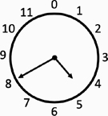

明智地选择不变式，设计就会简化。Choose your invariants wisely and it will simplify your design.

## 10.3. 将外在规约变为内在规约10.3. Making Intrinsic from Extrinsic

在第10.0.0节开发PriorityQueue模块时，决定除RemoveMin的非空前置条件外，所有函数规约都采用外在方式。优点是不必用证明元素使函数体变杂乱。缺点是函数无法依赖数据结构不变式。对某些函数而言，这并不重要。确实，第9章队列示例所有函数都能在完全不明确给出数据结构不变式的情况下工作。但对Braun树示例，这就有影响。看看为什么。In Section 10.0.0, we made the decision in the development of our PriorityQueue module that all specifications of our functions, except the non-emptiness precondition of RemoveMin, would be extrinsic. This brings the benefit of not having to clutter up the function bodies with proof elements. A drawback is that the functions cannot rely on the data-structure invariant. For some functions, this is not a big deal. Indeed, all the functions in the queue example in Chapter 9 work without spelling out a data-structure invariant at all. For the Braun tree example, it makes a difference. Let's see how.

### 10.3.0. 优化DeleteMin10.3.0. Optimizing DeleteMin

函数DeleteMin原先这样开头：We started off our function DeleteMin like this:

**function** DeleteMin(pq: PQueue): PQueue

**requires** !IsEmpty(pq)

{

**if** pq.left == Leaf || pq.right == Leaf **then**

pq.left

对于满足Braun树平衡条件的树，这个**if**测试有点冗余。任何Braun树都满足：For a tree that satisfies the Braun-tree balance condition, this **if** test is a bit redundant. Any Braun tree satisfies:

pq.left == Leaf ==> pq.right == Leaf

因此，**if**测试中的析取可简化为只有pq.right == Leaf。换言之，不存在只有左树是叶的情况，所以代码只检查右树即可。so the disjunction in the **if** test can be simplified to just pq.right == Leaf. In other words, there is no case where only the left tree is a leaf, so the code might as well just inspect the right tree.

## 习题10.4。Exercise 10.4.

表述并证明一个引理，说明Braun树平衡条件蕴含上述蕴含式。Formulate and prove a lemma that shows the Braun-tree balance condition to entail the implication above.

现在很想修改DeleteMin实现，使其改为这样开头It is now tempting to change our DeleteMin implementation to instead start off

**function** DeleteMin(pq: PQueue): PQueue

**requires** !IsEmpty(pq)

{

**if** pq.right == Leaf **then**

pq.left

**else if** pq.left.x <= pq.right.x **then** // error: .x requires pq.left

// to be a Node

但这样不行，因为函数下一行存在问题，这里也列出了。原则上，此DeleteMin函数可以对任意非空树调用，即使不满足Braun树平衡性质也可以，因此验证器抱怨代码试图访问pq.left的成员x。（瞧！刚刚给出了习题10.3的答案。）but that does not work, because of the next line of the function, which I included here. Since this DeleteMin function could, in principle, be called on any nonempty tree, even trees that do not satisfy the Braun-tree balance property, the verifier complains that the code tries to access member x of pq.left. (Well, there! I just gave you the answer to Exercise 10.3.)

为针对Braun树优化代码，需要用前置条件将其限制为Braun树。这是先前选择外在规约时未考虑到的。现在至少部分改变决定，为DeleteMin添加前置条件。To optimize our code for Braun trees, we need to give it a precondition that restricts it to Braun trees. That's what our decision of making the specifications extrinsic did not consider. Let's change that decision, at least partially, and add a precondition to DeleteMin.

**function** DeleteMin(pq: PQueue): PQueue

**requires** IsBalanced(pq) && !IsEmpty(pq)

{

**if** pq.right == Leaf **then**

pq.left

**else if** pq.left.x <= pq.right.x **then**

Node(pq.left.x, pq.right, DeleteMin(pq.left))

**else**

Node(pq.right.x, ReplaceRoot(pq.right, pq.left.x),

DeleteMin(pq.left))

}

修改规约后，即使使用简化的**if**测试，函数体也能验证。很好。但验证器抱怨RemoveMin中调用DeleteMin的地方。相应地修改其规约。可以尝试：With this change of specifications, the function body verifies even with the simplified **if** test. Good. But the verifier complains about the call to DeleteMin in RemoveMin. Let's change its specification accordingly. We might try:

**function** RemoveMin(pq: PQueue): (**int**, PQueue)

**requires** IsBalanced(pq) && !IsEmpty(pq)

这不行，因为模块导出RemoveMin而不导出IsBalanced。可以考虑也导出IsBalanced，但这会让优先队列客户承担又一个概念的负担。因此，进一步加强前置条件：This does not work, because our module exports RemoveMin, but not IsBalanced. We could consider exporting IsBalanced as well, but that would burden priority-queue clients with yet another concept. Instead, let's strengthen the precondition further:

**function** RemoveMin(pq: PQueue): (**int**, PQueue)

**requires** Valid(pq) && !IsEmpty(pq)

这样就成功了。现在已优化DeleteMin代码，加强其前置条件，并把规约变化传播到调用者。This does the trick. We have now optimized the code in DeleteMin, strengthened its precondition, and propagated its change in specifications to its callers.

### 10.3.1. 内在—外在规约的连续谱10.3.1. The intrinsic-extrinsic spectrum

为在DeleteMin中应用优化，必须加强某些规约。尽可能少地添加额外前置条件，最终在导出函数RemoveMin前置条件中加入Valid(pq)。从美感来说，这仍不理想，因为RemoveMin现在是唯一提及Valid的导出函数。换言之，模块接口陷入了混合使用内在与外在规约的情形。To apply the optimization in DeleteMin, we had to strengthen some specifications. We imposed as few additional preconditions as possible, culminating in the addition of Valid(pq) to the precondition of the exported function RemoveMin. Aesthetically, this leaves something to be desired, since RemoveMin is now the only one of the exported functions to mention Valid. In other words, we have gotten ourselves into a situation where the module interface uses a mix between intrinsic and extrinsic specifications.

可以考虑让所有规约完全内在化。即不在独立正确性引理中写函数规约，而直接写在函数上。采用此方式，函数RemoveMin声明为We could consider making all of the specifications fully intrinsic. In other words, instead of writing the function specifications in separate correctness lemmas, we could write the specifications on the functions directly. In this approach, function RemoveMin would be declared as

**function** RemoveMin(pq: PQueue): (**int**, PQueue)

**requires** Valid(pq) && !IsEmpty(pq)

**ensures var** (y, pq’) := RemoveMin(pq);

Valid(pq’) &&

IsMin(y, Elements(pq)) &&

Elements(pq’) + **multiset**{y} == Elements(pq)

内在与外在规约之间的选择是一个连续谱。设计空间中的一个中间点，是始终在内在规约中包含数据结构不变式Valid，但尽量省略其他功能正确性规约。采用此方式，函数RemoveMin声明为The choice between intrinsic and extrinsic specifications is a spectrum. An intermediate point in the design space is to always include the data-structure invariant, Valid, in the intrinsic specifications, but, to the extent possible, omit other functional-correctness specifications. In this approach, function RemoveMin would be declared as

**function** RemoveMin(pq: PQueue): (**int**, PQueue)

**requires** Valid(pq) && !IsEmpty(pq)

**ensures var** (y, pq’) := RemoveMin(pq);

Valid(pq’)

### 10.3.2. 对外内在，对内外在10.3.2. Externally intrinsic, internally extrinsic

无论选择内在—外在连续谱上的哪一点，只要函数包含非平凡后置条件，就会面临外在规约方式的缺点：不得不用额外引理调用污染函数体。但有一种分工方式，既提供简单的内在模块接口（或按所需程度内在化），又可将函数定义与正确性证明分开。做法是在外在规约函数之上，再构建一层内在规约函数。清晰的实现方式是将这两层写成独立模块。Regardless of which point of the intrinsic-extrinsic spectrum we choose, as soon as a function includes a nontrivial postcondition, we face the extrinsic-specification disadvantage of having to pollute the function body with additional lemma calls. But there is a division of labor that gives us a simple intrinsic (or as-intrinsic-as-we-want) module interface and yet lets us separate function definitions from their correctness proofs. It is to layer a suite of intrinsically specified functions on top of the extrinsically specified functions. A clean way to do this is to write the two layers as separate modules.

首先，把目前编写的PriorityQueue模块改名为PriorityQueueExtrinsic。First, let us change the name of the PriorityQueue module that we have written so far to PriorityQueueExtrinsic.

**module** PriorityQueueExtrinsic {

**export**

**provides** PQueue, Empty, IsEmpty, Insert, RemoveMin

**provides** Valid, Elements

**reveals** IsMin

**provides** EmptyCorrect, IsEmptyCorrect, InsertCorrect

**provides** RemoveMinCorrect

// the rest of the module as before…

}

接着定义另一个模块，作为PriorityQueueExtrinsic之上的一层，其中类型和函数直接用外在版本定义。此模块不包含正确性引理，因为将把规约写成函数的一部分。给它取直截了当的名称PriorityQueue，因为预期客户使用的就是它。下面展示其工作方式：Next, we define another module as a layer above PriorityQueueExtrinsic, where types and functions are defined directly in terms of the extrinsic counterparts. This module does not contain the correctness lemmas, because we are about to write the specifications as part of the functions. We give this module the straightforward name PriorityQueue, because we expect it to be the module that clients will use. Here, you can see how it works:

**module** PriorityQueue {

**export**

**provides** PQueue, Empty, IsEmpty, Insert, RemoveMin

**provides** Valid, Elements

**reveals** IsMin

**provides** Extrinsic

**import** Extrinsic = PriorityQueueExtrinsic

**type** PQueue = Extrinsic.PQueue

**ghost predicate** Valid(pq: PQueue) {

Extrinsic.Valid(pq)

}

**ghost function** Elements(pq: PQueue): **multiset**<**int**> {

Extrinsic.Elements(pq)

}

**ghost predicate** IsMin(m: **int**, s: **multiset**<**int**>) {

Extrinsic.IsMin(m, s)

}

**function** Empty(): PQueue {

Extrinsic.Empty()

}

**predicate** IsEmpty(pq: PQueue) {

Extrinsic.IsEmpty(pq)

}

**function** Insert(pq: PQueue, y: **int**): PQueue {

Extrinsic.Insert(pq, y)

}

**function** RemoveMin(pq: PQueue): (**int**, PQueue)

**requires** Valid(pq) && !IsEmpty(pq)

{

Extrinsic.RemoveMin(pq)

}

}

注意，模块导出集提供符号Extrinsic。如果希望像PriorityQueueExtrinsic一样揭示函数IsMin，这是必要的。（提供Extrinsic，还使我们可以揭示类型PQueue，而不只是提供它。当预期客户希望同时使用两个模块时，这在某些高级情形中很有用。）Note that the module export set provides the symbol Extrinsic. This is necessary if we want to, like in PriorityQueueExtrinsic, reveal function IsMin. (By providing Extrinsic, we also make it possible to reveal, not just provide, type PQueue. This can be useful in some advanced situations where we expect clients to want to use both modules.)

## 边栏10.1Sidebar 10.1

这里展示的模块PriorityQueue与PriorityQueueExtrinsic是同级声明。另一种组织方式，是把PriorityQueueExtrinsic写在模块PriorityQueue内部，成为嵌套模块。这样，还可删除PriorityQueue中引入局部名称Extrinsic的**import**声明，并将内部模块命名为Extrinsic。As I've shown them here, modules PriorityQueue and PriorityQueueExtrinsic are sibling declarations. An alternative organization is to make PriorityQueueExtrinsic a nested module, which you do by writing it inside module PriorityQueue. You can then also remove the **import** declaration in PriorityQueue that introduced the local name Extrinsic and give the inner module the name Extrinsic.

最后添加规约和证明。将PriorityQueueExtrinsic中每个正确性引理的规约复制到PriorityQueue的相应函数，再添加从函数到引理的调用。Finally, we add the specifications and proofs. This involves copying each correctness-lemma specification from PriorityQueueExtrinsic to the respective function in PriorityQueue and adding a call from the function to the lemma.

**function** Empty(): PQueue

**ensures var** pq := Empty();

Valid(pq) &&

Elements(pq) == **multiset**{}

{

Extrinsic.EmptyCorrect();

Extrinsic.Empty()

}

**predicate** IsEmpty(pq: PQueue)

**requires** Valid(pq)

**ensures** IsEmpty(pq) <==> Elements(pq) == **multiset**{}

{

Extrinsic.IsEmptyCorrect(pq);

Extrinsic.IsEmpty(pq)

}

**function** Insert(pq: PQueue, y: **int**): PQueue

**requires** Valid(pq)

**ensures var** pq’ := Insert(pq, y);

Valid(pq’) &&

Elements(pq’) == multiset{y} + Elements(pq)

{

Extrinsic.InsertCorrect(pq, y);

Extrinsic.Insert(pq, y)

}

**function** RemoveMin(pq: PQueue): (**int**, PQueue)

**requires** Valid(pq) && !IsEmpty(pq)

**ensures var** (y, pq’) := RemoveMin(pq);

Valid(pq’) &&

IsMin(y, Elements(pq)) &&

Elements(pq’) + **multiset**{y} == Elements(pq)

{

Extrinsic.RemoveMinCorrect(pq);

Extrinsic.RemoveMin(pq)

}

这个示例展示了如何在外在规约模块之上构建内在规约模块，其中使用完整的外在规约。如果希望选取内在—外在连续谱上的其他点，也遵循相同形式。In this example, where I showed how to layer an intrinsic-specification module on top of an extrinsic-specification module, I used the full extrinsic specifications. If you want a different point on the intrinsic-extrinsic spectrum, it would follow the same form.

## 10.4. 小结10.4. Summary

*不变式*是始终成立的条件。本章关心的不变式描述Braun树的一致性条件：堆性质和Braun树平衡性质。用此不变式证明了优先队列操作的功能正确性，还证明操作只产生平衡树。将不变式编码为谓词Valid。更确切地说，当给定骨架值满足所需数据结构不变式时，谓词Valid成立。随后在前置条件与后置条件中使用Valid()（第10.1.0节用于正确性引理，第10.3.2节用于内在规约函数）。An *invariant* is a condition that always holds. In this chapter, the invariant of interest described the consistency condition of Braun trees: the heap property and the Braun-tree balance property. We used this invariant to prove the functional correctness of priorityqueue operations, and also to prove that the operations produce only balanced trees. We encoded the invariant as a predicate Valid. More precisely, Valid is a predicate that holds when a given skeleton value satisfies the desired data-structure invariant. We then used Valid() in pre- and postconditions (for the correctness lemmas in Section 10.1.0 and for the intrinsically specified functions in Section 10.3.2).

在优先队列操作前置条件和后置条件中使用Valid()，使PriorityQueue模块客户知道存在有效性条件。模块接口只提供而不揭示Valid()，从而对不变式细节作抽象。实际上，这意味着客户无法从零自行构造树值，因为不知道Valid()要求什么，只能调用模块接口提供的操作获得优先队列值。这样，就创建了具有良好信息隐藏的已验证接口。By using Valid() in the pre- and postcondition of the priority-queue operations, clients of our PriorityQueue module are made aware of the existence of a validity condition. By only providing, not revealing, Valid() in the module interface, we abstract over the details of the invariant. In effect, this means that clients cannot fabricate their own tree values from scratch, because the client doesn't know what Valid() entails. Instead, clients can obtain priority-queue values only by calling the operations we provided in the module interface. In this way, we have created a verified interface with desirable information hiding.

如果认为数据结构始终具有某种性质，可以利用不变式检查。做法是编写并证明一个引理，说明数据结构不变式（Valid()）蕴含该性质（参见习题10.4）。If there's a property you think always holds of your data structure, you can use the invariant to check it. To do that, write and prove a lemma that the data-structure invariant (Valid()) implies the property of interest (see Exercise 10.4).

从程序结构与规约的角度看，此示例与许多提供不可变数据结构的模块的共同点，是用谓词Valid刻画数据结构不变式，并使用若干（这里是一个）抽象函数（如Elements）描述模块各种操作的效果。下一部分讨论可变数据结构时，会见到类似而稍复杂的模式。From the perspective of program structure and specification, what the example I showed has in common with so many other modules that provide immutable data structures is that it captures the data-structure invariant in a predicate Valid and uses some number (here, one) of abstraction functions (like Elements) to describe the effect of the various operations of the module. We'll see a similar, slightly more complicated pattern when we get to mutable data structures in the next Part of the book.

## 习题10.5。Exercise 10.5.

重新考虑习题9.4的BlockChain模块，将Balance函数结果类型从先前的**int**改为**nat**。要证明函数确实返回非负数，需要数据结构不变式。向模块添加谓词Revisit the BlockChain module of Exercise 9.4 and change the result type of the Balance function from the previous **int** to **nat**. To prove that the function does indeed return a non-negative number, you need to use a data-structure invariant. Add a predicate

**ghost predicate** Valid(ledger: Ledger)

如本章所做的一样。在Init、Deposit、Withdraw和Balance函数规约中使用该有效性谓词，并证明函数实现符合规约。照常编写并验证测试驱动程序，确保规约能以预期方式使用。to the module, like we have done in this chapter. Use this validity predicate in the specifications of the Init, Deposit, Withdraw, and Balance functions, and prove that the implementations of the functions meet their specifications. As usual, write and verify a test harness to make sure your specifications are usable in the way you'd expect.

## 注释Notes

是Aaron Stump介绍Agda验证的精彩入门书[120]让我认识了Braun树[24]。It was Aaron Stump's delightful introductory book on verification in Agda [120] that introduced me to Braun trees [24].

本章使用的有效性谓词（以及第16和17章将见到的谓词）让我们能描述数据结构的预期状态，而不向客户透露状态细节，从而实现信息隐藏。但能否隐藏更多？按当前模块接口的构造方式，客户永远无法获得无效骨架。那么，真有必要用有效性条件的存在来烦扰客户吗？一般而言，答案取决于客户是否有办法检测实现内部各部分的变更或相互作用。由于模块采用函数式编程，值不可变，事实上也可以隐藏Valid的存在。许多验证器（包括Dafny）为此支持*子集类型*（也称*谓词子类型*或*精化类型*），但本书不予介绍。The validity predicates we used in this chapter (and those we'll see in Chapters 16 and 17) let us describe the expected state of a data structure without divulging details of that state to clients. This achieves information hiding. But couldn't we hide even more? The way we created our module interface, a client will never be able to obtain a non-valid skeleton. So, then, is it really necessary to bother clients with the existence of a validity condition? The general answer to this question depends on if there are ways for clients to detect mutations in or interactions between parts of the implementation. Since we wrote our module using functional programming, where values are immutable, the answer is that we can in fact hide the existence of Valid as well. Many verifiers (including Dafny) support *subset types* (aka *predicate subtypes* or *refinement types*) for this purpose, but I won't cover them in this book.

一些验证语言和证明助手，包括Coq [16]、PVS [107]、Agda [22]、F* [53]和LiquidHaskell [123]，主要以这类子集类型为基础。在这些语言中，通常（甚至必须）将数据结构不变式表述为类型的一部分。Adam Chlipala的《*经认证的编程*》（Certified Programming）[27]讨论了此类编程与验证的高级形式。Some verification languages and proof assistants, including Coq [16], PVS [107], Agda [22], F* [53], and LiquidHaskell [123], are primarily based around such subset types. In those languages, it is customary (or even necessary) to formulate datastructure invariants as parts of types. Advanced forms of such programming and verification are treated in Adam Chlipala's book on *Certified Programming* [27].

# 第2部分 命令式程序Part 2 Imperative Programs

在命令式编程中，变量的值可以在程序执行期间改变。这让我们能够自然地表示现实生活中不断变化的状态，例如你的社交媒体联系人列表或机车的速度。这也意味着，我们不必立即得出计算所需的值，而可以分步进行，逐渐改变变量的值，直到得到所需的结果。命令式编程有时被誉为能够实现高效率，因为计算中的一个步骤可以只更新需要改变的部分，而不必复制状态中所有未改变的部分。In imperative programming, the value of a variable can be changed during the execution of the program. This gives us a natural way to represent evolving real-life state, like your social-media contact list or the speed of a locomotive. It also means that we don't have to immediately produce the desired value of a computation, but we can proceed in steps, gradually changing the values of variables until we obtain what we want. Imperative programming is sometimes hailed as achieving eﬃciency, because a step of a computation can update just what needs to be changed rather than making a copy of all pieces of the state that do not change.

在本部分中，我将介绍如何对三种命令式状态进行推理：局部变量、值的数组，以及动态分配且不断变化的数据结构。对这三者的推理都需要某种形式的*不变式*，就像我们在第10章中已经见到的数据结构不变式一样。In this Part, I will show you how to reason about three kinds of imperative state: local variables, arrays of values, and dynamically allocated, evolving data structures. Common to reasoning about each of these is some form of *invariant*, like the datastructure invariants we already saw in Chapter 10.

# 第11章 循环Chapter 11 Loops

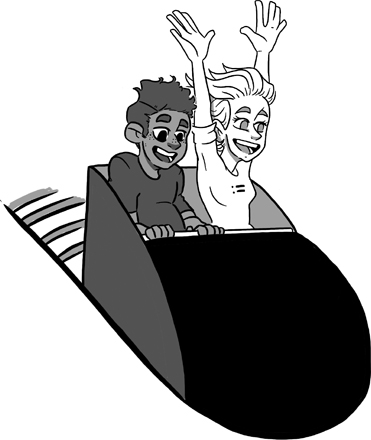

许多有趣的计算都可以描述为一系列步骤的重复。用于重复执行部分计算的常见结构是*循环*。循环结构有许多种形式，但在本章中——实际上，在整本书中——我只考虑一种循环形式，即 **while** 语句。Many interesting computations can be described as repetitions of steps. The common construct for repeating a part of a computation is the *loop*. There are many forms of loop constructs, but in this chapter—indeed, in this entire book—I will consider just one form of loop, the **while** statement.

对任何循环进行推理的核心都是*循环不变式*。我们先讨论循环规约，然后讨论循环实现、终止性以及许多例子。Central to reasoning about any loop is the *loop invariant*. Let's start with loop specifications, then loop implementations, termination, and many examples.

## 11.0. 循环规约11.0. Loop Specifications

循环的规约由两部分组成。*循环不变式*限制循环可以探索的状态空间。*循环守卫*控制循环何时继续执行步骤、何时停止。The specification of a loop consists of two parts. The *loop invariant* restricts the state space that the loop is allowed to explore. The *loop guard* controls when the loop continues performing steps and when it stops doing so.

在循环的前状态中，有一项证明义务：不变式必须成立。我将其称为*循环使用证明义务*。循环的*效果*是从一个不变式成立的状态，转移到一个不变式与守卫的否定都成立的状态。In the pre-state of a loop, there is a proof obligation that the invariant hold. I'll refer to this as the *loop-use proof obligation*. The *effect* of a loop is to go from one state where the invariant holds to a state where both the invariant and the negation of the guard hold.

### 11.0.0. 非技术性例子11.0.0. Non-technical examples

我们来看看这是如何运作的。下面是一个说明性的循环规约：Let's see how this works. Here's an illustrative loop specification:

**while** *not in Seattle*

**invariant** *on the train*

**while** 关键字后面是守卫，**invariant** 关键字后面是不变式。循环还有一个*循环体*，只要循环守卫成立，就会重复执行循环体。不过，在本节中，我将有意省略循环体，让我们只关注循环*规约*。What follows the **while** keyword is the guard, and what follows the **invariant** keyword is the invariant. A loop also has a *loop body*, whose execution is repeated as long as the loop guard holds. However, throughout this section, I will intentionally omit the loop body so that we can focus just on the loop *specification*.

根据循环使用证明义务，要使用这个循环，你最初必须在火车上。因此，你需要让循环前的代码把你带上火车。循环结束后，由不变式和守卫的否定可知，你既在火车上，又在西雅图。因此，我想你会让循环之后的代码使你下车，开始享受在这座城市的一天。According to the loop-use proof obligation, you must be on the train initially in order to use this loop. So, you'll want to arrange for the code before the loop to get you on the train. After the loop, by the invariant and the negation of the guard, you are both on the train and in Seattle. So, I expect you'll want to arrange for the code that follows the loop to get you off the train and start enjoying your day in the city.

注意，不变式只说你在火车上，所以根据循环规约，进入和退出循环时，你可能处于不同的车厢。还要注意，只要你在火车上，就允许你在西雅图开始这个循环。也就是说，进入循环时必须成立的是循环不变式，循环守卫的值无关紧要。循环之后，不变式与守卫的否定都成立。Note that the invariant only says you're on the train, so by the loop specification, you may be in different cars on entry and exit of the loop. Also, note that you are allowed to start the loop in Seattle, as long as you are on the train. That is, it is the loop invariant that must hold on entry to the loop, and the value of the loop guard is irrelevant. After the loop, both the invariant and the negation of the guard hold.

再看一个例子：Here's another example:

**while** *homework is not done*

**invariant** *awake*

要使用这个循环，你起初必须醒着（即使你的作业碰巧已经完成）。循环结束后，你既醒着，又完成了作业。将这个循环规约与下面的规约比较一下：To use this loop, you must start off awake (even if your homework happens to be done already). After the loop, you find yourself both awake and with your homework done. Compare that loop specification with the following:

**while** *awake*

**invariant** *homework is not done*

要使用这个循环，你起初必须尚未完成作业。循环结束后，你已经睡着，而作业仍未完成。To use this loop, you must start off with your homework not done. After the loop, you find yourself asleep and your homework is still not done.

### 11.0.1. 循环规约的 Floyd 逻辑11.0.1. Floyd logic for loop specifications

我已经用文字陈述了循环规约的规则。我们可以像第2章那样，用 Floyd 逻辑形式化地陈述它。对于布尔表达式 B 和 J，循环规约的语义由下面这个 Hoare 三元组给出：I've stated the rule for loop specifications in words. We can state it formally in Floyd logic, as we did in Chapter 2. For boolean expressions B and J, the semantics of a loop specification is given by this Hoare triple:

{{ J }}

**while** B

**invariant** J

{{ J && !B }}

它的意思是，要使用这个循环，就必须证明其不变式最初成立。这就是循环使用证明义务。循环之后，你就能得知不变式和循环守卫的否定成立。It says that to use the loop, you must prove that its invariant holds initially. This is the loop-use proof obligation. After the loop, you get to find out that the invariant and the negation of the loop guard hold.

### 11.0.2. 数值例子11.0.2. Numeric examples

下面是一个使用整数的循环规约示例：Here's an example loop specification that uses integers:

**while** x < 300

**invariant** x % 2 == 0

要使用这个循环，你必须证明 x 为偶数。循环之后，你可以假定 x 仍为偶数，并且 300 <= x。To use this loop, you must prove that x is even. After the loop, you get to assume that x is still even and that 300 <= x.

这个例子又如何呢？What about this one?

**while** x % 2 == 1

**invariant** 0 <= x <= 100

这个循环带来的证明义务是：x 必须在 0 到 100 的范围内。循环之后，你可以得知 x 是 0 到 100 范围内的偶数。This loop comes with the proof obligation that x be in the range from 0 through 100. After the loop, you get to find out that x is an even number from 0 through 100.

下面这个循环规约前面有一条赋值语句，后面有一条断言：Here's a loop specification preceded by an assignment and followed by an assertion:

x := 2;

**while** x < 50

**invariant** x % 2 == 0

**assert** 50 <= x && x % 2 == 0;

要求进入循环时 x % 2 == 0 成立的循环使用证明义务可以得到证明，因为此时 x 的值为 2。循环之后，我们知道不变式成立，守卫的否定也成立。这恰好就是断言中的条件，所以断言也可以得到证明。The loop-use proof obligation that x % 2 == 0 hold on entry is provable, because x has the value 2 at that time. After the loop, we get to know that the invariant holds and that the negation of the guard holds. This is exactly the condition in the assertion, so the assertion is provable as well.

再看一个例子：Here's another example:

x := 0;

**while** x % 2 == 0

**invariant** 0 <= x <= 20

**assert** x == 19; // not provable

进入循环时，x 为 0，因此 x 必须在 0 到 20 范围内的证明义务得到满足。为了证明断言，我们需要证明On entry, x is 0, so the proof obligation that x be in the range from 0 through 20 is met. To prove the assertion, we need to prove

0 <= x <= 20 && x % 2 != 0 ==> x == 19

我们无法证明这个蕴含式。例如，退出循环时 x 可能为 3，因为 3 是奇数，而且在 0 到 20 的范围内。We cannot prove this implication. For example, x could be 3 on exit from the loop, since 3 is odd and is in the range from 0 through 20.

## 练习11.0。Exercise 11.0.

对于下面每一种循环规约的使用情况，指出循环使用证明义务是否满足，以及能否证明循环之后的断言成立。For each of the following uses of loop specifications, indicate whether or not the loop-use proof obligation is met and whether or not the assertion following the loop can be proved to hold.

| a) | x := 0; **while** x != 100 **invariant true** **assert** x == 100; | b) | x := 20; **while** 10 < x **invariant** x % 2 == 0 **assert** x == 10; |
| --- | --- | --- | --- |
| c) | x := 20; **while** x < 20 **invariant** x % 2 == 0 **assert** x == 20; | d) | x := 3; **while** x < 2 **invariant** x % 2 == 0 **assert** x % 2 == 0; |
| e) | **if** 50 < x < 100 { **while** x < 85 **invariant** x % 2 == 0 **assert** x < 85 && x % 2 == 1; } | f) | **if** 0 <= x { **while** x % 2 == 0 **invariant** x < 100 **assert** 0 <= x; } |
| g) | x := 0; **while** x < 100 **invariant** 0 <= x < 100 **assert** x == 25; |  |  |

### 11.0.3. 达到相等11.0.3. Attaining equality

循环中一种常见情况是：我们希望一个变量从某个区间的一端开始，在到达该区间另一端时终止。例如，我们可能用 0 初始化变量 i，并希望一直循环，直到 i 达到 100。在这种情况下，我们通常把变量 i 称为*循环索引*。A common situation with loops is that we want a variable to start at one end of an interval and terminate at the other end of that interval. For example, we may initialize a variable i with 0 and want to loop until i has reached 100. In such situations, we often refer to variable i as the *loop index*.

下面就是这样的一个程序片段：Here is such a program fragment:

i := 0;

**while** i != 100

**invariant** 0 <= i <= 100

**assert** i == 100;

仅凭循环守卫的否定，我们就能证明断言。因此，这个断言的证明不依赖于不变式。例如，在下面的程序中，该断言也可以得到证明：From the negation of the loop guard alone, we can prove the assertion. So, the proof of this assertion does not depend on the invariant. For example, the assertion is also provable in the following program:

i := 0;

**while** i != 100

**invariant true**

**assert** i == 100;

第一个循环规约还有一种变体：Another variation of the first loop specification is

i := 0;

**while** i < 100

**invariant** 0 <= i <= 100

**assert** i == 100;

这个断言也可以得到证明。但与上面两个例子不同，这里的守卫是 i < 100，因此仅凭守卫的否定（100 <= i）无法证明断言。这时就需要用到不变式 i <= 100。根据 100 <= i（守卫的否定）和 i <= 100（不变式），我们可以得出 i == 100，从而证明断言。This assertion is also provable. But here, unlike in the two examples above, the guard is i < 100, so it is not possible to prove the assertion from just the negation of the guard (100 <= i). This is where the invariant i <= 100 comes in. From 100 <= i (the negation of the guard) and i <= 100 (the invariant), we can conclude i == 100, which makes the assertion provable.

作为第四个例子，考虑As a fourth example, consider

i := 0;

**while** i < 100

**invariant true**

**assert** i == 100; // not provable

这个断言无法得到证明，因为循环之后我们只知道 **true** && 100 <= i。This assertion is not provable, because all we know after the loop is **true** && 100 <= i.

从这四个小例子可以得出：要编写一个达到特定值的循环规约，有多种方法。如果循环守卫是 i != 100，那么我们立即就知道循环后 i 为 100。如果循环守卫是 i < 100，那么循环不变式还需要规定 i <= 100，我们才能在循环后得出 i == 100。The conclusion from these four little examples is that there are several ways to write a loop specification that reaches a particular value. If the loop guard is i != 100, then we immediately know that i is 100 after the loop. If the loop guard is i < 100, then the loop invariant also needs to stipulate i <= 100 in order for us to conclude i == 100 after the loop.

此外，根据我的经验，理解这四个例子以及它们各自为何能够或不能通过验证，是使用循环的关键。到目前为止，我所说的一切都来自循环*规约*（不变式和守卫）。事实上，对循环进行推理用的是循环规约，而不是循环体。在 11.1节介绍循环体时，请不要忘记这一点。Moreover, in my experience, understanding these four examples and why each one verifies or does not verify is key to working with loops. Everything I've said so far comes from the loop *specification* (the invariant and the guard). Indeed, reasoning about a loop uses the loop specification, not the loop body. Try not to forget this when I introduce loop bodies in Section 11.1.

## 练习11.1。Exercise 11.1.

对每个程序，给出循环后 **int** 类型的 i 的一个可能值，以表明该断言无法得到证明。For each program, give a possible value of i of type **int** after the loop that shows that the assertion is not provable.

| a) | i := 0; **while** i < 100 **invariant** 0 <= i **assert** i == 100; | b) | i := 100; **while** 0 < i **invariant true** **assert** i == 0; |
| --- | --- | --- | --- |
| c) | i := 0; **while** i < 97 **invariant** 0 <= i <= 99 **assert** i == 99; | d) | i := 22; **while** i % 5 != 0 **invariant** 10 <= i <= 100 **assert** i == 55; |

## 练习11.2。Exercise 11.2.

对练习11.1中的每个程序，加强其不变式，使它既在进入循环时成立，又足以证明断言。For each program in Exercise 11.1, strengthen the invariant so that the invariant both holds on entry to the loop and suﬃces to prove the assertion.

### 11.0.4. 变量之间的关系11.0.4. Variable relations

涉及多个变量时，循环会有趣得多。下面这个循环规约中的循环不变式关联了两个变量：Loop are much more interesting when they involve more than one variable. Here's a loop specification where the loop invariant relates two variables:

x, y := 0, 0;

**while** x < 300

**invariant** 2 * x == 3 * y

**assert** 200 <= y;

根据循环规约的规则，不变式中所述的 x 与 y 之间的关系在循环后成立，守卫的否定，即 300 <= x. 也成立。这使我们能够在循环后得出 200 <= y，从而证明断言。Following our rule for loop specifications, the relation between x and y stated in the invariant holds after the loop, as does the negation of the guard, that is, 300 <= x. This lets us conclude 200 <= y after the loop, so we can prove the assertion.

再看一个例子：Here's another example:

x, y := 0, 191;

**while** !(0 <= y < 7)

**invariant** 7 * x + y == 191

**assert** x == 191 / 7 && y == 191 % 7;

这个程序计算 191 和 7 的整数商及模数，这一点由（可以证明的）断言予以确认。这个循环规约的一种变体是This program computes the integer quotient and modulus of 191 and 7, as the (provable) assertion confirms. A variation of this loop specification is

x, y := 0, 191;

**while** 7 <= y

**invariant** 0 <= y && 7 * x + y == 191

**assert** x == 191 / 7 && y == 191 % 7;

这个不变式将 y 限制为非负值，因此我们可以简化守卫。This invariant constrains y to non-negative values, so we can simplify the guard.

作为最后一个例子，下面的程序计算前 33 个自然数的和：As a final example, the following program computes the sum of the first 33 natural numbers:

n, s := 0, 0;

**while** n != 33

**invariant** s == n * (n - 1) / 2

借助一个熟悉的算术恒等式，不变式表达了 s 是前 n 个自然数的和。循环之后，我们可以推断 n 为 33，因此也知道 s 是前 33 个自然数的和。Through a familiar arithmetic identity, the invariant expresses that s is the sum of the first n natural numbers. After the loop, we can infer that n is 33, and therefore we also know that s is the sum of the first 33 natural numbers.

### 11.0.5. 循环框架11.0.5. Loop frames

考虑下面的循环规约，其中循环计算出的 r 是 N 的整数平方根：Consider the following loop specification, where the loop computes r to be the integer square root of N:

r, N := 0, 104;

**while** (r+1)*(r+1) <= N

**invariant** 0 <= r && r*r <= N

**assert** 0 <= r && r*r <= N < (r+1)*(r+1);

在做其他事情之前，让我们先停下来欣赏一下这段程序的美妙之处。r 是 N 的整数平方根，意味着 N 位于从 r 的平方到 r+1 的平方的范围内，且 r 本身非负。我们希望这三个不等式在循环之后都可以得到证明。在循环规约中表达这一点的一种方法是：将其中两个条件放入不变式，将第三个条件的否定放入循环守卫。啊，真美妙！Before doing anything else, let's pause for a moment to appreciate the beauty of this program fragment. For r to be the integer square root of N means that N lies in the range from the square of r to the square of r+1, and r itself is non-negative. We want these three inequalities to be provable after the loop. One way to express that in a loop specification is to put two of the conditions into the invariant and to put the negation of the third condition into the loop guard. Aaaaaah, what a beaut!

我们用断言的各个组成部分构造循环规约，确保了例子中的断言可以得到证明。那么，我们能否得出循环之后 r 为 10 呢？如果循环之后 N 仍为 104，那么当然，r 将为 10。但循环规约并没有说 N 仍会是 104。例如，这个循环规约允许退出循环时 r 和 N 分别为 2 和 5。By constructing the loop specification from the pieces of the assertion, we made sure the assertion in our example is provable. So, then, can we conclude that r is 10 after the loop? If N is still 104 after the loop, then sure, r will be 10. But the loop specification does not say N will still be 104. For example, the loop specification allows r and N on exit from the loop to be 2 and 5, respectively.

由此我们发现，循环规约有一个明显的遗漏：它没有说明哪些变量可以改变，哪些必须保持不变。规约中说明什么可以修改、什么必须保持不变的部分称为*框架*——在这里，更准确地说，是*循环框架*。我们可以在循环规约已有的循环不变式和循环守卫之外，再添加一个显式的循环框架。不过，先不这样做，因为就在下一节，我打算通过查看循环实现来确定循环框架。因此，现在只需记住，循环框架也是规约的一部分；除非我另有说明，否则隐式的循环框架允许修改所有局部变量。From this realization, we see that our loop specifications have a glaring omission: they don't say which variables are allowed to be changed and which must stay the same. The part of a specification that talks about what can be modified and what has to be unchanged is called a *frame*—in our context, more precisely, a *loop frame*. We could add an explicit loop frame to the loop invariant and loop guard that are already part of a loop specification. But let's not, because already in the next section, I have a plan for figuring out the loop frame by looking at the loop implementation. So, for now, let's just remember that there is such a thing as a loop frame that is part of the specification, and unless I say otherwise, the implicit loop frame allows all local variables to be modified.

## 11.1. 循环实现11.1. Loop Implementations

如果你以前写过循环（我*确实*假定你写过），那么读完上一节后，你可能感到困惑，想知道我所说的循环是不是你熟悉的循环。是的，它们是一样的。但到目前为止，我只讨论了循环*规约*，而你以前写的可能是循环*实现*。让我们把这两个概念结合起来。现在我将引入你熟悉的东西，但你可别忘记刚刚学到的循环规约——我一定会提醒你的。If you've written loops before (which I *am* assuming you have), then you may be puzzled after reading the previous section, wondering if the loops I'm talking about are the loops you're familiar with. Yes, they are the same. But so far, I've only talked about loop *specifications*, and the loops you've written are probably loop *implementations*. Let's combine these two notions. As I now bring in the familiar, don't you go forgetting about what you just learned about loop specifications—I'll be sure to remind you.

循环之所以得名，是因为它通过重复一系列步骤来实现其规约。具体而言，只要循环守卫成立，循环就重复执行其*循环体*。循环体就是循环的*实现*。在语法上，这个实现写在循环规约之后的花括号内。A loop derives its name from the fact that its specification is carried out through a repetition of steps. In particular, a loop repeats the execution of its *loop body* for as long as the loop guard holds. The loop body is the *implementation* of the loop. Syntactically, this implementation is given in curly braces after the loop specification.

### 11.1.0. 商与模数11.1.0. Quotient modulus

作为第一个例子，我们回到上一节中计算 191 和 7 的商与模数的循环。下面是该循环的规约，还包括循环前的初始化赋值以及循环后的断言：As our first example, let's return to the loop in the previous section for computing the quotient and modulus of 191 and 7. Here is the specification for that loop, including an initializing assignment before the loop and an assertion after the loop:

x, y := 0, 191;

**while** 7 <= y

**invariant** 0 <= y && 7 * x + y == 191

**assert** x == 191 / 7 && y == 191 % 7;

循环体是一系列语句，在其初始状态下循环守卫成立的前提下，它维持循环不变式。也就是说，从一个不变式和守卫都成立的状态开始，循环体应产生一个不变式成立的状态。让我们思考一下，在商与模数程序中，可以通过哪些方式做到这一点。也就是说，思考一下下面这个 Hoare 三元组中的 ? 处可以写什么：The loop body is a sequence of statements that maintains the loop invariant, given that the loop guard holds in its initial state. That is, starting from a state where both the invariant and the guard hold, the body is to produce a state where the invariant holds. Let's think of some ways we can do this for the quotient-modulus programs. That is, let's think of what we can write for the ? in the following Hoare triple:

{{ 0 <= y && 7 * x + y == 191 && 7 <= y }}

?

{{ 0 <= y && 7 * x + y == 191 }}

#### 一个循环体A loop body

替换 ? 的一种方法是将 x 增加 1，或许还需要改变 y。使用2.3节中赋值语句的最弱前置条件计算方法，以及2.3.1节中程序证明的记账式记法，我们得到：One way to replace the ? is to increase x by 1, and maybe we'll need to change y as well. Using the weakest-precondition computations for assignment in Section 2.3 and the bookkeeping notation for program proofs from Section 2.3.1, we have:

{{ 0 <= y && 7 * x + y == 191 && 7 <= y }}

?

{{ 0 <= y && 7 * (x + 1) + y == 191 }}

x := x + 1

{{ 0 <= y && 7 * x + y == 191 }}

中间的公式可以化简：The formula in the middle can be simplified:

7 * (x + 1) + y == 191

=

7 * x + 7 + y == 191

如果在这个公式中用 y - 7 替换 y，得到的条件就与 Hoare 三元组开头的条件相同。因此有：If we substitute y - 7 for y in this formula, we get the same condition as at the start of the Hoare triple. So, we have:

{{ 0 <= y && 7 * x + y == 191 && 7 <= y }}

{{ 0 <= y - 7 && 7 * x + 7 + (y - 7) == 191 }}

y := y - 7

{{ 0 <= y && 7 * x + 7 + y == 191 }}

{{ 0 <= y && 7 * (x + 1) + y == 191 }}

x := x + 1

{{ 0 <= y && 7 * x + y == 191 }}

最好再检查一遍这个计算，尤其是因为代换的方向很容易令人混淆。从这些行中的*最后*一行开始*向上*阅读，每当遇到赋值语句，就用赋值右侧的表达式替换被赋值的变量（将 x 替换为 x + 1，将 y 替换为 y - 7）；每当两行之间没有程序语句时，就需要检查前一行是否蕴含后一行。（必要时可复习2.3.1节。）It's best to double-check this computation, especially because it's easy to get confused with the direction of the substitution. Starting from the *last* of these lines and reading *upward*, whenever we come across an assignment, we replace the variable being assigned with the right-hand side of the assignment (replacing x by x + 1, and replacing y by y - 7), and whenever there are two lines with no program statement in between, we need to check that the first of the two implies the second. (Review Section 2.3.1 as needed.)

做法就是这样，但也许你觉得有点过于形式化。我们再用精确但非形式化的方式想一遍。我们需要写一条语句，维持条件 7 * x + y == 191（以及各种范围条件，等等）。如果将 x 增加 1，那么从这个公式可以清楚地看出，我们需要将 y 减少 7。这就是维持不变式的含义。That's how it's done, but maybe this felt a bit formal. Let's think about it again, precisely but informally. We are supposed to write a statement that maintains the condition 7 * x + y == 191 (along with various range conditions, yada yada). If we increase x by 1, then it's clear from this formula that we need to decrease y by 7. This is what it means to maintain an invariant.

我们的程序如下：Here's our program:

x, y := 0, 191;

**while** 7 <= y

**invariant** 0 <= y && 7 * x + y == 191

{

y := y - 7;

x := x + 1;

}

**assert** x == 191 / 7 && y == 191 % 7;

#### 一步跳到答案Leap to the answer

商与模数程序的循环体不止一种实现方法。下面这个 Hoare 三元组展示了维持不变式的另一种方法：There's more than one way to implement the loop body for the quotient-modulus program. Here's a Hoare triple that shows a different way to maintain the invariant:

{{ 0 <= y && 7 * x + y == 191 && 7 <= y }}

{{ **true** }}

{{ 0 <= 2 && 7 * 27 + 2 == 191 }}

x, y := 27, 2

{{ 0 <= y && 7 * x + y == 191 }}

这样，我们就发现了实现循环的另一种方式：So, we have discovered another way to implement our loop:

x, y := 0, 191;

**while** 7 <= y

**invariant** 0 <= y && 7 * x + y == 191

{

x, y := 27, 2;

}

**assert** x == 191 / 7 && y == 191 % 7;

#### 速度加倍Going twice as fast

我们再多研究一下这个第一个带循环体的程序，考虑一种行不通的做法。试着把两次循环体执行合并为一次怎么样？我们不将 x 增加 1、将 y 减少 7，而是试着将 x 增加 2、将 y 减少 14。这样，表达循环实现的证明义务的 Hoare 三元组就是：Let's dwell on this first program with a loop body some more, to consider something that does not work. How about we try to combine two loop bodies into one? Instead of incrementing x by 1 and decrementing y by 7, let's try incrementing x by 2 and decrementing y by 14. The Hoare triple that expresses the proof obligation of the loop implementation is then:

{{ 0 <= y && 7 * x + y == 191 && 7 <= y }}

{{ 14 <= y && 7 * x + y == 191 }} // error: does not follow

// from the previous annotation

{{ 0 <= y - 14 && 7 * (x + 2) + (y - 14) == 191 }}

x, y := x + 2, y - 14

{{ 0 <= y && 7 * x + y == 191 }}

其中，我在提出的赋值语句上方又添加了两条注释。我们的“更快”更新确实维持了关系 7 * x + y == 191。不过，它产生了证明义务 14 <= y，而这一点不能从最上面一行推出。因此，这种加快循环的尝试并不正确。where I added two more annotations above the proposed assignment statement. Our “quicker” update does maintain the relation 7 * x + y == 191. However, it gives rise to the proof obligation 14 <= y, which does not follow from the top line. So, this attempt to speed up the loop is not correct.

## 练习11.3。Exercise 11.3.

在循环体中引入一条 **if** 语句，其中一个分支为 x, y := x + 2, y - 14，另一个为 x, y := x + 1, y - 7。为使循环正确，你需要在 **if** 语句中使用什么守卫条件？Introduce an **if** statement in the body of the loop, where one branch is x, y := x + 2, y - 14 and the other is x, y := x + 1, y - 7. What guard condition do you need in the **if** statement to make the loop correct?

#### 维持任何条件的最简单方法The easiest way to maintain anything

如果我们只需建立一个已经成立的条件，那么没有比什么也不做更简单的办法了。的确，这可以维持任何循环不变式。但无论重复执行这样的循环体多少次，都不会使我们更接近循环守卫不再成立的状态。因此，除非守卫一开始就不成立，否则这样的循环永远不会终止。If all we have to do is establish a condition that already holds, then there's no simpler way to proceed than to do nothing. Indeed, this would maintain any loop invariant. But no number of repetitions of such a loop body would get us any closer to reaching a state where the loop guard no longer holds. So, unless the guard didn't hold in the first place, such a loop would never terminate.

循环终止性很重要，不过我将把细节留到 11.2节。Loop termination is important, but I'll postpone the details until Section 11.2.

### 11.1.1. 形式化地描述循环不变式的维持11.1.1. Being formal about maintaining the loop invariant

对于循环For a loop

**while** B

**invariant** J

{

Body

}

维持循环不变式的证明义务，在 Floyd 逻辑中由下面这个 Hoare 三元组表达：the proof obligation for maintaining the loop invariant is captured in Floyd logic by the following Hoare triple:

{{ J && B }}

Body

{{ J }}

注意，这项证明义务中没有重复执行 Body。Hoare 三元组给你的假设就是 J && B，仅此而已！如果需要更强的条件才能证明 Body 之后 J 成立，那么就需要加强不变式。当然，如果将循环不变式从 J 加强为某个 J’，那么还必须证明 Body 之后成立的是 J’（而不只是 J）。Note that there is no repetition of Body in this proof obligation. The Hoare triple gives you the assumption J && B and that's it! If you need something stronger to prove that J holds after Body, then you need to strengthen the invariant. Of course, if you strengthen the loop invariant from J to some J’, then you also need to prove that J’ (not just J) holds after Body.

除了这项关于维持不变式的证明义务外，循环还有一项关于终止性的证明义务。我们将在 11.2节看到它。In addition to this proof obligation about maintaining the invariant, there's a loop proof obligation about termination. We'll see it in Section 11.2.

### 11.1.2. 计算总和11.1.2. Computing sums

我们再看上一节的一个例子，即求前 33 个自然数之和的例子。其规约如下：Let's do one more example from the previous section, the one that sums up the first 33 natural numbers. Here is the specification:

**while** n != 33

**invariant** s == n * (n - 1) / 2

要实现这个循环，我们需要填写下面这个 Hoare 三元组中的 ?：To implement this loop, we need to fill in the ? in the following Hoare triple:

{{ s == n * (n - 1) / 2 && n != 33 }}

?

{{ s == n * (n - 1) / 2 }}

将 n 增加 1 似乎很合理。我们来推算一下，这需要对 s 做什么改变：Incrementing n by 1 seems reasonable. Let's work out what change that entails for s:

(s == n * (n - 1) / 2)**[**n := n + 1**]**

= { *substitution* }

s == (n + 1) * n / 2

=

s == (n*n + n) / 2

=

s == (n*n - n + 2*n) / 2

=

s == (n*n - n) / 2 + 2*n / 2

=

s == n * (n - 1) / 2 + n

由于根据循环不变式，s 最初为 n * (n - 1) / 2，我们看到需要将 s 增加 n。因此，完整程序如下，其中还包括循环前对 n 和 s 的赋值，以使不变式最初成立：Since, by the loop invariant, s starts off as n * (n - 1) / 2, we see that we need to increment s by n. So, our whole program, including an assignment to n and s before the loop that establishes the invariant initially, is:

n, s := 0, 0;

**while** n != 33

**invariant** s == n * (n - 1) / 2

{

s := s + n;

n := n + 1;

}

## 练习11.4。Exercise 11.4.

为上面的循环编写一个不同的（但仍然正确的）初始化赋值。Write a different (but still correct) initializing assignment for the loop above.

## 练习11.5。Exercise 11.5.

为下面的循环规约编写初始化赋值和循环实现：Write an initializing assignment and a loop implementation for the following loop specifications:

| a) | **while** x < 300 **invariant** x % 2 == 0 | b) | **while** x % 2 == 1 **invariant** 0 <= x <= 100 |
| --- | --- | --- | --- |

## 练习11.6。Exercise 11.6.

考虑下面的程序片段：Consider the following program fragment:

x := 0;

**while** x < 100

{

x := x + 3;

}

**assert** x == 102;

编写一个循环不变式，使它最初成立、由循环体维持，并使你能够证明循环后的断言。Write a loop invariant that holds initially, is maintained by the loop body, and allows you to prove the assertion after the loop.

### 11.1.3. 推断循环框架11.1.3. Loop frames inferred

在11.0.5节中，我提到循环规约还需要循环框架，即说明循环允许修改什么、必须使什么保持不变。现在，关于这一点，我有两件事要说。In Section 11.0.5, I mentioned that a loop specification also needs a loop frame, that is, an indication of what the loop is allowed to modify and what it must leave unchanged. At this time, I have two things to say about that.

第一，Dafny 中的输入参数是不可变的。因此显然，循环规约中提到的任何输入参数（其实也包括循环规约中没有提到的任何输入参数）都不会被循环改变。One thing is that in-parameters in Dafny are immutable. Thus, it is clear that any in-parameter mentioned in a loop specification (or, for that matter, any in-parameter omitted from a loop specification) is not changed by the loop.

第二，Dafny 确实有办法确定哪些局部变量（以及输出参数）在循环框架内。它不是根据循环规约的某个显式部分来确定，而是查看循环实现。更准确地说，如果循环体在语法上包含对某个局部变量的赋值，那么该变量就在循环框架内。在实践中，这意味着：一旦写好了循环规约和循环体，验证器就知道，凡是未在循环体中被赋值的局部变量，在循环后的值都与循环前相同。对于循环确实赋值的任何局部变量，你都应在循环不变式中说明有关它的某些性质——否则，验证器在循环后就没有关于它的任何信息。The other thing is that Dafny does have a way to work out which local variables (and out-parameters) are inside the loop frame. It does so not from an explicit part of the loop specification, but instead from peering into the loop implementation. More precisely, a local variable is inside the loop frame if the loop body syntactically contains an assignment to the variable. What this means in practice is that once you've written the loop specification and loop body, the verifier knows that any local variable that's not assigned in the loop body will have the same value after the loop as it did before the loop. For any local variable that your loop does assign to, you'll want to say something about that variable in the loop invariant—otherwise, the verifier won't have any information about it after the loop.

下面的例子说明了这一点：The following example illustrates:

**method** LoopFrameExample(X: **int**, Y: **int**)

**requires** 0 <= X <= Y

{

**var** i, a, b := 0, X, Y;

**while** i < 100 {

i, b := i + 1, b + X;

}

**assert** a == X;

**assert** Y <= b; // not provable without an invariant for the loop

}

由于循环体中没有对 a 赋值，而且 X 是输入参数（所以当然也没有对 X 赋值），循环后的断言 a == X 可以得到证明。相反，b 在循环体中被赋值，因此如果没有关于 b 的循环不变式，验证器在循环后就对 b 一无所知。要证明第二个断言，需要将Since there is no assignment to a in the loop body and X is an in-parameter (so, of course there's no assignment to X, either), the assertion a == X is provable after the loop. On the contrary, b is assigned in the loop body, so without a loop invariant about b, the verifier knows nothing about b after the loop. To prove the second assertion, you need to add

**invariant** Y <= b

或or

**invariant** b == Y + i * X

加入循环规约。由于 X 是输入参数，无须再添加不变式 0 <= X，就能证明这样的循环不变式。to the loop specification. Such a loop invariant is provable without the further invariant that 0 <= X, since X is an in-parameter.

## 11.2. 循环终止性11.2. Loop Termination

循环实现还有一项证明义务，即证明终止性。当然，必须证明循环体本身会终止。例如，循环体对外围方法的任何递归调用，都必须按照我们在第3章中见过的方式证明会终止。此外，还必须证明循环体的重复执行最终会结束。换言之，我们要防止无限重复，也就是*无限循环*。There's one more proof obligation for loop implementations, which is to show termination. Of course, the loop body itself must be shown to terminate. For example, any recursive call from the loop body to the enclosing method must be shown to terminate, in the way we saw back in Chapter 3. In addition, we must show that the repetitions of the loop body eventually come to an end. In other words, we want to prevent infinite repetitions, or *infinite looping*.

防止无限循环的方法是用良基序中的元素为循环迭代加标签，正如通过用良基序中的元素为函数和方法的活动记录加标签来防止无限递归一样。不过，这里不是证明从调用者到被调用者的递减，而是证明从一次迭代到下一次迭代的递减。具体做法是在走过循环的“回边”时计算下一次迭代的标签。更简单地说，我们检查循环体是否使循环的终止度量递减。Infinite looping is prevented by labeling the loop iterations by elements of a well-founded order, just as infinite recursion is prevented by labeling the activation records of functions and methods by elements of a well-founded order. But instead of showing a decrease from a caller to a callee, we show a decrease from one iteration to the next. This is accomplished by computing the next iteration's label at the time the loop's “back edge” is taken. Stated more simply, we check that the body causes a decrease of the loop's termination metric.

循环的终止度量使用 **decreases** 子句声明。对于循环The loop's termination metric is declared using a **decreases** clause. For a loop

**while** B

**invariant** J

**decreases** D

{

Body

}

终止性的证明义务用 Hoare 三元组表述为：the proof obligation of termination, phrased as a Hoare triple, is:

{{ J && B }}

**ghost var** d<sub>0</sub> := D;

Body

{{ d<sub>0</sub> ≻ D }}

为了方便地记录进入循环体时 D 的值，以便在 Hoare 三元组的后置条件中再次引用它，我引入了幽灵局部变量 d<sub>0</sub>。这个 Hoare 三元组说明，我们必须证明 d<sub>0</sub> 大于循环体执行后的 D 的值。As a convenient way to record the value of D on entry to the loop body, so that we can refer to it again in the Hoare-triple postcondition, I introduced a ghost local variable d<sub>0</sub>. The Hoare triple says that we must show that d<sub>0</sub> exceeds the value of D after the loop body.

### 11.2.0. 商与模数循环的终止性11.2.0. Termination of quotient modulus

在 11.1.0节中，我们考虑了一个规约为计算 191 和 7 的商与模数的循环的几种实现。我们来检查一下对该循环规约的几种实现尝试的终止性。In Section 11.1.0, we considered several implementations of the loop that is specified to compute the quotient and modulus of 191 and 7. Let's check termination of some attempted implementations of that loop specification.

#### 简单的循环体Simple body

最直接的程序的循环体是The body of our most straightforward program is

y := y - 7;

x := x + 1;

由于 y 在递减，我们就选它作为终止度量。这样，需要证明Since y is being decreased, let's choose it as our termination metric. We then have to prove

{{ 0 <= y && 7 * x + y == 191 && 7 <= y }}

**ghost var** d<sub>0</sub> := y;

y := y - 7;

x := x + 1;

{{ d<sub>0</sub> ≻ y }}

我们处理的是整数，因此根据整数上的良基序 ≻ 的定义（3.2节），必须证明：We're working with integers, so by the definition of the well-founded order ≻ on integers (Section 3.2), we have to prove:

y < d<sub>0</sub> && 0 <= d<sub>0</sub>

第一个合取项成立，因为 y == d<sub>0</sub> - 7；第二个合取项由不变式 0 <= y 推出（也可由守卫 7 <= y 推出）。完成了！The first conjunct follows because y == d<sub>0</sub> - 7, and the second conjunct follows from the invariant 0 <= y (and it also follows from the guard 7 <= y). Done!

下面是整个循环的写法——包括规约、实现和初始化赋值：Here's how we write the whole loop—specification, implementation, and initializing assignment:

x, y := 0, 191;

**while** 7 <= y

**invariant** 0 <= y && 7 * x + y == 191

**decreases** y

{

y := y - 7;

x := x + 1;

}

#### 快速的循环体Quick body

回顾一下商与模数循环的一步跳到答案的实现：Recall the leap-to-the-answer implementation of the quotient-modulus loop:

x, y := 27, 2;

这里递减的是什么呢？为了更清楚地看出这一点，下面用 Hoare 三元组的形式给出证明义务，两个问号处应填写相同的表达式：What is it that decreases here? To see it more clearly, here is the proof obligation in Hoare-triple form, where the two question marks should be filled in with the same expression:

{{ 0 <= y && 7 * x + y == 191 && 7 <= y }}

ghost var d<sub>0</sub> := ?;

x, y := 27, 2;

{{ d<sub>0</sub> ≻ ? }}

注意，Hoare 三元组允许我们从 7 <= y 开始。因此，**decreases** y 也能用于证明这个循环的终止性。Notice that the Hoare triple allows us to start with 7 <= y. Therefore, **decreases** y works to prove termination of this loop, too.

#### 反转方向Switching directions

下面是此前尚未尝试过的一种循环实现：Here is an attempt at implementing the loop that we didn't try before:

**while** 7 <= y

**invariant** 0 <= y && 7 * x + y == 191

{

x, y := x - 1, y + 7;

}

这个循环体不是递增 x、递减 y，而是反过来做。这仍然维持了不变式。但要证明终止性，就需要 x 的下界或 y 的上界。两者我们都没有。事实上，如果 y 起初满足守卫，那么它会一直满足守卫，所以这个程序确实不会终止。Instead of incrementing x and decrementing y, this loop body does it the other way around. This still maintains the invariant. But to prove termination, we would need a lower bound on x or an upper bound on y. We have neither. Indeed, if y starts off satisfying the guard, then it always will, so this program really won't terminate.

我们可以*证明*这个循环*不会*终止。一种方法是初始化 y，使其满足守卫，并将 7 <= y 添加为不变式：We can *prove* that this loop does *not* terminate. One way to do that is to initialize y to satisfy the guard and to add 7 <= y as an invariant:

x, y := 0, 191;

**while** 7 <= y

**invariant** 0 <= y && 7 * x + y == 191

**invariant** 7 <= y

{

x, y := x - 1, y + 7;

}

（与多个 **requires** 和 **ensures** 子句类似，编写多个 **invariant** 子句，等同于编写一个将所有条件合取起来的子句。）这个程序虽然不会终止，但确实维持了不变式。更一般地说，只要出现不变式蕴含守卫的情况，就意味着循环不会终止。<sup>3</sup>(Analogous to multiple **requires** and **ensures** clauses, writing multiple **invariant** clauses is the same as writing one that conjoins all the conditions.) Though it does not terminate, this program does maintain the invariant. More generally, whenever we have a situation where the invariant implies the guard, that means the loop will not terminate.<sup>3</sup>

### 11.2.1. 循环的默认 decreases 子句11.2.1. Default decreases clauses for loops

在3.4节中，我解释过，如果你没有为递归函数或方法提供 **decreases** 子句，Dafny 会提供一个默认子句。对于没有显式编写 **decreases** 子句的循环，Dafny 也会提供一个默认子句。In Section 3.4, I explained that Dafny provides a default **decreases** clause for recursive functions or methods, if you don't supply one. Dafny also supplies a default **decreases** clause for any loop where you don't explicitly write one.

Dafny 构造默认 **decreases** 子句的规则简单得近乎笨拙，却又出人意料地有效。简而言之，如果循环守卫是算术比较 E < F 或 E <= F，那么默认子句就是Dafny's rule for constructing a default **decreases** clause is foolishly simple and surprisingly effective. In a nutshell, if the loop guard is an arithmetic comparison E < F or E <= F, then the default is

**decreases** F - E

如果循环守卫是算术比较 E != F，那么默认子句就是 E 与 F 之差的绝对值：And if the loop guard is an arithmetic comparison E != F, then the default is the absolute difference between E and F:

**decreases if** E < F **then** F - E **else** E - F

即使只有这些简单规则，你也会发现，无须你做任何事情，Dafny 就能证明很大一部分会终止的循环。Even with these simple rules, you'll find that Dafny will prove a large share of your terminating loops without you having to do anything.

你不必知道构造默认 **decreases** 子句的确切规则，但在 Dafny IDE 中，将鼠标悬停在循环的 **while** 关键字上，就可以轻松查看 Dafny 得出了什么。如果不喜欢默认的 **decreases** 子句（大概只有默认子句不足以证明循环终止时才会如此），你只需自行提供一个即可。You don't need to know the exact rules for how the default **decreases** clause is constructed, but you can easily inspect what Dafny came up with by hovering over the **while** keyword of a loop in your Dafny IDE. If you don't like the default **decreases** clause (which probably happens only if the default is not good enough to prove termination of your loop), you can just supply your own.

## 11.3. 循环规则总结11.3. Summarizing the Loop Rule

我们把循环的所有证明义务汇集到一起。对于循环Let's collect all the proof obligations of a loop in one place. For a loop

**while** B

**invariant** J

**decreases** D

{

Body

}

使用该循环的上下文将它视为the context that uses the loop views it as

{{ J }}

**while** B

**invariant** J

**decreases** D

{

Body

}

{{ J && !B }}

这与 Body 无关（其实也与 D 无关），而循环实现的正确性归结为证明which has nothing to do with Body (or with D, for that matter), and the correctness of the loop implementation comes down to proving

{{ J && B }}

**ghost var** d<sub>0</sub> := D;

Body

{{ J && d<sub>0</sub> ≻ D }}

这与循环结构会反复执行 Body 这一事实无关。which has nothing to do with the fact that the loop construct will repeatedly execute the Body.

## 练习11.7。Exercise 11.7.

对于下面的每个方法，编写一个循环不变式和一个（显式的）**decreases** 子句，使你能够证明该方法。For each of the following methods, write a loop invariant and an (explicit) **decreases** clause that allow you to prove the method.

**method** UpWhileLess(N: **int**) **returns** (i: **int**)

**requires** 0 <= N

**ensures** i == N

{

i := 0;

**while** i < N {

i := i + 1;

}

}

**method** UpWhileNotEqual(N: **int**) **returns** (i: **int**)

**requires** 0 <= N

**ensures** i == N

{

i := 0;

**while** i != N {

i := i + 1;

}

}

**method** DownWhileNotEqual(N: **int**) **returns** (i: **int**)

**requires** 0 <= N

**ensures** i == 0

{

i := N;

**while** i != 0 {

i := i - 1;

}

}

**method** DownWhileGreater(N: **int**) **returns** (i: **int**)

**requires** 0 <= N

**ensures** i == 0

{

i := N;

**while** 0 < i {

i := i - 1;

}

}

你应当做好自行编写循环不变式的准备，不过 Dafny 也会为你做一点点推断。如果你惊讶于其中两个例子无须编写任何循环不变式，那是因为它为你推断出了不变式。尽管如此，还是请你也亲自将它们写出来。You should expect to have to write your loop invariants, but Dafny does a wee bit of inference for you. If you're surprised that you don't need to write any loop invariant for two of these examples, it's because it infers them for you. Still, go ahead and write them yourself, too.

## 11.4. 整数平方根11.4. Integer Square Root

本章最后再看一个例子，即我们在 11.0.5节中简略接触过的整数平方根程序。我们从方法规约开始：I'll wrap up this chapter with one more example, the integer-square-root program that we got a brief taste of in Section 11.0.5. We'll start with a method specification:

**method** SquareRoot(N: **nat**) **returns** (r: **nat**)

**ensures** r * r <= N < (r + 1) * (r + 1)

注意，我将 N 限制为自然数，以免陷入尝试计算负数平方根的困境。我还将 r 声明为 **nat** 类型，这样就不必在后置条件以及稍后的循环不变式中写出 0 <= r。Note that I restricted N to be a natural number, so that we won't get stuck trying to compute the square root of a negative number. I also declared r to be of type **nat**, which saves us from having to write 0 <= r in the postcondition and, later, in the loop invariant.

### 11.4.0. 解决该问题的一种技巧11.4.0. A technique for solving the problem

在接下来的几章中，我们会遇到许多用于设计循环以解决某些形式问题的技巧。下面是第一个这样的技巧。During the course of the next chapters, we'll come across a number of techniques for designing loops to solve problems of certain forms. Here is the first such technique.

## **循环设计技巧11.0。**（省去一个合取项）**Loop design technique 11.0.** (Omit a conjunct)

要解决形式为 A && B 的问题，选择 A 作为循环不变式，选择 !B 作为循环守卫。也就是说，使用如下循环规约：To solve a problem of the form A && B, pick the loop invariant to be A and pick the loop guard to be !B. That is, use a loop specification like this:

**while** !B

**invariant** A

平方根问题由两个合取项组成。像之前见过的那样，我们使用 r * r <= N 作为循环不变式，使用 N < (r + 1) * (r + 1) 的否定作为循环守卫。为了使不变式最初成立，可以将 r 设为 0：The square-root problem consists of two conjuncts. As we had seen before, let's use r * r <= N as the loop invariant and let's use the negation of N < (r + 1) * (r + 1) as the loop guard. To establish the invariant initially, we can set r to 0:

{

r := 0;

**while** (r + 1) * (r + 1) <= N

**invariant** r * r <= N

我们可以通过递增 r 来实现这个循环。We can implement this loop by an increment to r.

{

r := r + 1;

}

}

全部就这些！得到的程序对 r 的正确值进行线性搜索。That's all there is! The resulting program is a linear search for the right value of r.

### 11.4.1. 更高效的程序11.4.1. A more eﬃcient program

程序的每次迭代都会求表达式 (r + 1) * (r + 1) 的值。如果考虑效率，我们可以改为根据上一次迭代中该表达式的值来计算它。不变式可以帮助我们确保程序变换正确。我们将借助我喜欢称之为*许愿*的方式来做。过程如下：Every iteration of our program evaluates the expression (r + 1) * (r + 1). If eﬃciency is a concern, we may instead consider computing the expression from the value of the expression in a previous iteration. Invariants can help us make sure we transform the program correctly. We'll do it through what I like to call a *wish*. It goes like this:

我希望有一个变量 s，它的值始终为 (r + 1) * (r + 1)。如果有，就可以把循环守卫改为 s <= N。我们用循环不变式记录这个愿望，因为循环不变式会产生证明义务，促使我们把愿望变成现实。I wish we had a variable s whose value was always (r + 1) * (r + 1). If we did, we could change the loop guard to be s <= N. Let's keep track of our wish in a loop invariant, because a loop invariant gives us proof obligations that will prompt us to turn the wish into reality.

**invariant** s == (r + 1) * (r + 1)

很好。现在循环规约有了这个不变式，我们的一项义务就是使它最初成立。由于 r 最初为 0，循环不变式直接告诉我们，必须将 s 初始化为 1。Very well. Now that our loop specification has this invariant, one of our obligations is to establish it initially. Since r is initially 0, the loop invariant directly tells us that we must initialize s to 1.

**var** s := 1;

另一项证明义务是在循环体中维持不变式。循环体递增 r，因此我们可以计算该赋值相对于新不变式的最弱前置条件。也就是说，我们将从所需的循环不变式*反向推导*。这会告诉我们，在对 r 赋值之前，必须对 s 建立什么条件。The other proof obligation is to maintain the invariant in the body. The body increments r, so we can compute the weakest precondition of that assignment with respect to our new invariant. That is, we will *work backward* from the desired loop invariant. This will tell us what we have to establish about s before the assignment to r.

{{ s == (r + 1 + 1) * (r + 1 + 1) }}

r := r + 1

{{ s == (r + 1) * (r + 1) }}

根据算术运算，有：By arithmetic, we have:

(r + 1 + 1) * (r + 1 + 1)

=

r*r + 4*r + 4

=

r*r + 2*r + 1 + 2*r + 3

=

(r + 1) * (r + 1) + 2*r + 3

这是个好消息，因为根据不变式，我们知道进入循环体时 s 为 (r + 1) * (r + 1)。因此，只需将 s 增加 2 * r + 3。This is good news, because we know, by the invariant, that s is (r + 1) * (r + 1) on entry to the loop body. So, all we need to do is increment s by 2 * r + 3.

s := s + 2*r + 3;

我们必须考虑如何使新不变式最初成立，以及如何维持它。We had to think about establishing the new invariant initially and about maintaining it.

因此，计算整数平方根的最终程序如下：So, here is our final program to compute the integer square root:

**method** SquareRoot(N: **nat**) **returns** (r: **nat**)

**ensures** r * r <= N < (r + 1) * (r + 1)

{

r := 0;

**var** s := 1;

**while** s <= N

**invariant** r * r <= N

**invariant** s == (r + 1) * (r + 1)

{

s := s + 2*r + 3;

r := r + 1;

}

}

构造这个程序时使用的技巧可概括如下：The technique we used in constructing the program is captured as follows:

## **循环设计技巧11.1。**（许愿式编程）**Loop design technique 11.1.** (Programming by wishing)

如果预先计算出某个量 Q 能使问题更简单，那么就引入一个新变量 q，目标是建立并维持不变式 q == Q。If a problem can be made simpler by having a precomputed quantity Q, then introduce a new variable q with the intention of establishing and maintaining the invariant q == Q.

我将在12.1节进一步介绍这个技巧。I'll expand on this technique in Section 12.1.

## 11.5. 小结11.5. Summary

循环分为两部分：规约和实现。循环规约本身分为三个部分：A loop has two parts, a specification and an implementation. The loop specification itself has three parts:

- 循环守卫，控制循环何时继续重复执行the loop guard, which controls when the loop's repetition continues
- 循环不变式，约束循环迭代可以探索的状态the loop invariant, which constrains the state the loop iterations may explore
- 循环框架，通常是隐式的the loop frame, which usually is implicit

当你*使用*循环规约时，必须满足循环使用证明义务（即必须证明循环不变式最初成立）。作为回报，你可以得知，循环之后不变式和循环守卫的否定成立。When you *use* a loop specification, you have to meet the loop-use proof obligation (that is, you have to prove that the loop invariant holds initially). In return, you get to find out that, after the loop, the invariant and the negation of the loop guard hold.

循环实现是称为循环体的块语句。当你*实现*循环时，必须证明：从循环守卫成立的状态开始，循环体维持循环不变式。为确保循环的重复执行最终结束，还必须证明循环体使某个终止度量递减。The loop implementation is a block statement known as the loop body. When you *implement* a loop, you must show that the loop body maintains the loop invariant from a state where the loop guard holds. To ensure that the loop's repetitions eventually end, you must also show that the loop body decreases some termination metric.

许多循环不变式符合一些常见模式。本章中，我指出了两个这样的模式（作为循环设计技巧），接下来的章节还会继续指出这些模式。它们提供了一些技巧，供你在自行设计循环和不变式以解决问题时尝试使用。Many loop invariants fall into common patterns. In this chapter, I identified two such patterns (as Loop Design Techniques), and I will continue to point out such patterns in chapters to come. These patterns give you techniques that you can try when designing your own loops and invariants to solve problems.

循环是命令式编程的标志，循环不变式是程序证明的关键部分。现在你已经见过若干循环和不变式示例，最好回顾一下本章开头没有循环体的循环规约。如果初读时，你觉得*忽略*循环体来对循环进行推理很奇怪，那么现在你或许已经开始体会到，循环规约如何将对循环*使用*的推理与对循环*实现*的推理区分开来。Loops are a hallmark of imperative programming and loop invariants are a critical part of program proofs. Now that you have seen several example loops and invariants, it's a good idea to review the body-less loop specifications at the beginning of this chapter. If on your first reading you had found it strange to reason about a loop by *ignoring* its body, you may now start to appreciate how the loop specification separates the concerns of reasoning about the *use* of the loop from the concerns of reasoning about the *implementation* of the loop.

## 练习11.8。Exercise 11.8.

使用第6章的数据类型 List 和函数 Length，编写一个循环，构造一个将给定值 d 重复 n 次的 List。将返回的列表长度为 n 作为方法的后置条件加以证明。Using datatype List and function Length from Chapter 6, write a loop that constructs a List with a given value d repeated n times. Prove as a postcondition of the method that the returned list has length n.

## 练习11.9。Exercise 11.9.

编写一个方法 Duplicate，接收一个 List（见第6章），返回一个长度为其两倍的列表。新列表的元素可以是你喜欢的任何值——本练习只关心列表长度。证明返回列表确实是原列表两倍长这一后置条件。Write a method Duplicate that takes a List (see Chapter 6) and returns a list twice as long. The elements of the new list can be anything you'd like—this exercise is concerned only with the length of the list. Prove the postcondition that the returned list is indeed twice as long as the original.

## 注释Notes

不变式在程序证明中无处不在。例如，我们在第10章中见过数据结构不变式，还将在第16章中见到对象不变式。本章介绍了循环不变式。从学习角度看，循环为内化不变式概念提供了一个友好的试验场，因为你无须编写很多行代码，就能试验不同的循环不变式。利用本章及下一章的简单例子，理解如何使用不变式对程序进行推理，而无须知道循环执行了多少次迭代。Invariants are ubiquitous in program proofs. For example, we saw data-structure invariants in Chapter 10 and we'll see object invariants in Chapter 16. This chapter introduced loop invariants. From a learning perspective, loops offer a friendly playground for internalizing the concept of invariants, because you don't have to write many lines of code to experiment with different loop invariants. Use the simple examples of this chapter and the next to develop an understanding of how invariants are used to reason about programs without needing to know how many iterations a loop performs.

尽管循环不变式是对循环进行推理的最常见方式，但对于重复的命令式行为，也有其他推理方式。Eric Hehner 的一篇经典论文 [60] 表达了这方面的一种观点。Although loop invariants are the most prevalent way to reason about loops, there are other ways to reason about repeated, imperative behavior. A sentiment about this is captured in a classic paper by Eric Hehner [60].

<sup>3</sup>除非循环还有其他出口，例如由 **return** 或 **break** 语句提供的出口。<sup>3</sup>Unless there is another exit from the loop, as would be facilitated by a **return** or **break** statement.

# 第12章 递归规约，迭代程序Chapter 12 Recursive Specifications, Iterative Programs

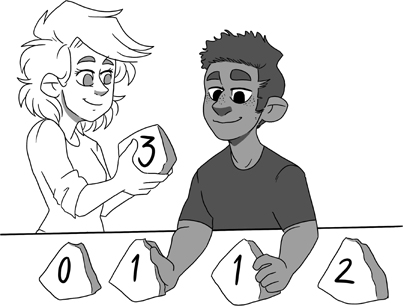

我们经常在方法规约中使用函数，而函数通过递归构建。如果用循环实现这样的方法，那么循环不变式也会使用函数来表达。本章给出一些例子，说明以这种方式将递归与迭代联系起来时会出现的问题。We often use functions in method specifications, and functions are built up using recursion. If we implement such a method using a loop, then the loop invariant is also going to be expressed using functions. In this chapter, I give some examples that demonstrate issues that arise when you connect recursion and iteration in this way.

## 12.0. 迭代式斐波那契计算12.0. Iterative Fibonacci

在3.1节中，我将著名的斐波那契数列In Section 3.1, I defined the famous Fibonacci sequence

0, 1, 1, 2, 3, 5, 8, …

定义为一个递归函数：by a recursive function:

**function** Fib(n: **nat**): **nat** {

**if** n < 2 **then** n **else** Fib(n - 2) + Fib(n - 1)

}

查看这个函数，很容易看出它正确定义了斐波那契数列：从 0 和 1 开始，之后的每个数都定义为前两个斐波那契数之和。然而，如果尝试在运行时以这种方式计算斐波那契数，速度会慢得惊人。我们来使用循环编写一个高效得多的版本（计算 Fib(*n*) 需要 𝒪(*n*) 次加法运算）。It is simple to inspect this function to see that it defines the Fibonacci sequence correctly: it starts with 0 and 1, and all subsequent numbers are defined as the sum of the preceding two Fibonacci numbers. Attempting to compute Fibonacci numbers this way at run time, however, would be disastrously slow. Let's write a far more eﬃcient version (𝒪(*n*) addition operations for Fib(*n*)) using a loop.

我们使用函数 Fib 为方法 ComputeFib 编写规约：We use function Fib to specify our method, ComputeFib:

**method** ComputeFib(n: **nat**) **returns** (x: **nat**)

**ensures** x == Fib(n)

注意，Fib 只是规约的一部分，在执行 ComputeFib 时不会求值。换言之，**ensures** 子句是幽灵代码，它说明我们希望验证什么，并会被编译器擦除。事实上，既然我们不打算在编译后的程序中直接使用函数 Fib，将它声明为幽灵函数就很合理；本章后文中，我确实会将这种仅用于规约的函数声明为幽灵函数。Note that Fib is just part of the specification and will not be evaluated when ComputeFib is executed. In other words, the **ensures** clause is ghost, explains what we want to verify, and is erased by the compiler. In fact, since we don't intend for function Fib to be used directly in a compiled program, it would make sense to declare it as ghost; indeed, in the rest of this chapter, I will declare such specification-only functions as ghost.

我们将使用一个循环来实现 ComputeFib，其循环索引 i 的范围从 0 到 n。因此，初始化和循环规约如下：We will implement ComputeFib using a loop with loop index i, which will range from 0 through n. The initialization and loop specification thus looks like this:

{

x := 0;

**var** i := 0;

**while** i != n

**invariant** 0 <= i <= n

**invariant** x == Fib(i)

}

这个循环规约说明，循环之后 i == n，且 x == Fib(n)。这表明我们的方向正确——我们已经将实现方法的问题归结为实现循环的问题。This loop specification says that, after the loop, i == n and x == Fib(n). This tells us we're on the right track—we have reduced the problem of implementing the method to a problem of implementing the loop.

刚才的做法，是根据所需后置条件设计循环规约的一项基础技巧：将后置条件中的常量 n 替换为循环索引 i。该技巧概括如下：What we just did is a cornerstone technique of designing a loop specification from a desired postcondition: we replaced the constant n in the postcondition with the loop index i. Here is a summary of that technique:

## **循环设计技巧12.0。**（用变量替换常量）**Loop design technique 12.0.** (Replace constant by variable)

要让循环建立条件 …C…，其中 C 是整个循环期间保持不变的表达式，可以使用一个变量 k，由循环改变它，直到它等于 C，并将 …k… 作为循环不变式。For a loop to establish a condition …C…, where C is an expression that is held constant throughout the loop, use a variable k that the loop changes until it equals C, and make …k… a loop invariant.

将这个循环设计技巧用于我们的程序时，常量 C 对应输入参数 n，变量 k 对应循环索引 i。Applied to our program, the constant C in this loop design technique is our inparameter n and the variable k is our loop index i.

在实现循环时，我们立即可以看出，赋值As part of implementing the loop, we immediately see that an assignment

i := i + 1;

能够维持第一个循环不变式，并使我们能够证明终止性。will maintain the first loop invariant and will let us prove termination.

循环体还必须更新 x。要高效地做到这一点，可以跟踪两个连续的斐波那契数，而不是只跟踪一个。我们将一个存储在 x 中，另一个存储在局部变量 y 中。不过，现在有两种选择。设计循环时，我们可以采用The loop body must also update x. The idea that will let us do this eﬃciently is to keep track of not just one Fibonacci number, but two consecutive Fibonacci numbers. We'll store one in x, and let's store the other in a local variable y. But now we have a choice. We can either design our loop with

**invariant** x == Fib(i) && y == Fib(i + 1)

也可以采用or design it with

**invariant** y == Fib(i - 1) && x == Fib(i)

当 i 为 0 时，后者没有良好的定义（因为 Fib 被定义为接收一个 **nat**）。可以将不变式写成下面这样来补救：The latter is not well-defined when i is 0 (since Fib is defined to take a **nat**). We can salvage the situation by writing that invariant as

**invariant** (i == 0 || y == Fib(i - 1)) && x == Fib(i)

这不是一个好主意。如果一开始就使用更复杂的不变式，最终很可能得到更复杂的程序。循环不变式体现了我们所编写循环的设计，因此在尝试编写循环体之前先写出循环不变式，可以更早发现一些设计缺陷。This is not a good idea. If we start off with a more complicated invariant, chances are we'll end up with a more complicated program. The loop invariant captures the design of the loop we're writing, so by writing down the loop invariant first, before attempting to write the loop body, we can detect some design flaws earlier.

所以，我们采用 y 是 x 之后那个斐波那契数的不变式。引入 y 并将其初始化，以建立不变式：So, let's use the invariant where y is the Fibonacci number after x. We introduce y and initialize it to establish the invariant:

**var** y := 1;

我们已经决定在循环中递增 i，因此，为了得到更新 i 之前所需的条件，要从循环不变式反向推导。正如之前见过的那样，在希望对 i 赋值后成立的条件中，用 i + 1 替换 i，就能得到所需条件。结果是We have already decided to increment i in the loop, so to obtain the condition we need before the update of i, we work backward from the loop invariant. As we've seen before, we get there by replacing i by i + 1 in the condition we want after the assignment to i. This gives us

{{ x == Fib(i) && y == Fib(i + 1) && i != n }}

?

{{ x == Fib(i + 1) && y == Fib(i + 1 + 1) }}

i := i + 1

{{ x == Fib(i) && y == Fib(i + 1) }}

其中，? 标明需要更新 x 和 y 的位置。我们希望对 x 赋值，使其等于 Fib(i + 1)。这很容易，因为可以看出，在 ? 之前，y 就具有该值。同时，我们希望对 y 赋值，使其等于 Fib(i + 2)。根据 Fib 的定义，这等于 Fib(i) + Fib(i + 1)，而这两项在 ? 之前分别存储在 x 和 y 中。因此，现在我们知道，应将 ? 替换为where the ? shows where we need to update x and y. We want to assign x so that it equals Fib(i + 1). This is easy, since we can see that y has that value before the ?. At the same time, we want to assign y so that it equals Fib(i + 2). By the definition of Fib, this is the same as Fib(i) + Fib(i + 1), and those two terms are found in x and y before the ?. So, we now know that the ? should be replaced by

x, y := y, x + y;

我们对 ComputeFib 的实现完成了。为提醒你刚才做了什么，这里给出整个方法，其中还包括证明中使用的 Hoare 三元组注释（终止性部分除外，在这个程序中 Dafny 会自动处理它）：Our implementation of ComputeFib is complete. For the sake of reminding you of what we just did, I'm showing you the whole method here, including Hoare-triple annotations we used in the proof (except the pieces for termination, which Dafny takes care of automatically in this program):

**method** ComputeFib(n: **nat**) **returns** (x: **nat**)

**ensures** x == Fib(n)

{

{{ **true** }}

x := 0;

**var** i := 0;

**var** y := 1;

{{ 0 <= i <= n && x == Fib(i) && y == Fib(i + 1) }}

**while** i != n

**invariant** 0 <= i <= n

**invariant** x == Fib(i) && y == Fib(i + 1)

{

{{ 0 <= i <= n && x == Fib(i) && y == Fib(i + 1) && i != n }}

{{ 0 <= i < n && x == Fib(i) && y == Fib(i + 1) }}

{{ 0 <= i < n && y == Fib(i + 1) && x + y == Fib(i) + Fib(i + 1) }}

x, y := y, x + y;

{{ 0 <= i < n && x == Fib(i + 1) && y == Fib(i) + Fib(i + 1) }}

{{ 0 <= i < n && x == Fib(i + 1) && y == Fib(i + 2) }}

{{ 0 <= i + 1 <= n && x == Fib(i + 1) && y == Fib(i + 1 + 1) }}

i := i + 1;

{{ 0 <= i <= n && x == Fib(i) && y == Fib(i + 1) }}

}

{{ 0 <= i <= n && x == Fib(i) && y == Fib(i + 1) && i == n }}

{{ x == Fib(n) }}

}

## 练习12.0。Exercise 12.0.

（进阶）编写一个命令式程序，仅使用 𝒪(log *n*) 次算术运算来计算 Fib(*n*)。(Advanced) Write an imperative program that computes Fib(*n*) using only 𝒪(log *n*) arithmetic operations.

## 12.1. 斐波那契数的平方12.1. Fibonacci Squared

本节将运用强大的*许愿式编程*技巧（循环设计技巧11.1），让不变式引导我们逐步改进程序。之前引入一项小优化时，我们已经使用过这个技巧（11.4.1节）。In this section, I employ the powerful technique of *programming by wishing* (Loop Design Technique 11.1) to let invariants guide us in gradually improving a program. We already used this technique in introducing a little optimization (Section 11.4.1).

我们将实现一个计算斐波那契数平方的方法：We'll implement a method that computes the square of a Fibonacci number:

**method** SquareFib(N: **nat**) **returns** (x: **nat**)

**ensures** x == Fib(N) * Fib(N)

假设程序将在一台不支持乘法、只支持加法的机器上执行。因此，我们不使用乘法来实现这个方法（但可以在规约中自由使用乘法，因为规约不会被编译）。我知道，我们刚刚实现了 ComputeFib，并在其中作出了一些设计决策；不过，这里我们重新开始，看看许愿技巧如何发挥作用。Suppose our program will execute on a machine that has no support for multiplication, only addition. So, let's implement the method without using multiplication (but we are free to use multiplication in specifications, since they are not compiled). I know we just implemented ComputeFib, where we made certain design decisions, but let's start afresh here to see how the wishing technique plays out.

### 12.1.0. 简单的起点12.1.0. A simple start

我们知道用变量替换常量的技巧，因此引入循环索引 n，并编写一个循环不变式，将后置条件中的常量 N 替换为 n：We know the technique of replacing a constant by a variable, so let's introduce a loop index n and write a loop invariant where the postcondition's constant N is replaced by n:

{

x := 0;

**var** n := 0;

**while** n != N

**invariant** 0 <= n <= N

**invariant** x == Fib(n) * Fib(n)

}

循环体将递增 n，因此我们反向推导，确定应给 x 赋什么值：The loop body will increment n, so let's work backward to figure out what to assign to x:

{{ x == Fib(n + 1) * Fib(n + 1) }}

n := n + 1

{{ x == Fib(n) * Fib(n) }}

显然，在更新 n 之前，需要将 x 设为 Fib(n + 1) 的平方。在这样的情况下，通常可以展开作用于 n + 1 的函数，得到另一个用作用于 n 的函数表达的式子。但对 Fib 不能这样做，因为其递推关系是根据前*两个*值 Fib(n - 1) 和 Fib(n) 定义的，而如果 n - 1 为负数，就不能对它调用 Fib。Apparently, we need to set x to the square of Fib(n + 1) before we update n. In a situation like this, it is often possible to expand the function applied to n + 1 and obtain another expression in terms of the function applied to n. But we can't do that with Fib, because its recurrence is defined in terms of the previous *two* values, Fib(n - 1) and Fib(n), and if n - 1 is negative, we can't call Fib on it.

### 12.1.1. 许一个愿望12.1.1. A wish

别担心。我们就希望已经计算出了 Fib(n + 1) 的平方，并存储在某个变量中，比如 y。将愿望记为不变式，并找到满足该不变式的 y 的初始值后，更新后的程序为No worries. Let's just wish we had the square of Fib(n + 1) already computed in a variable, say y. Recording our wish as an invariant and finding an initial value for y that satisfies that invariant, our updated program is

x := 0;

**var** n, y := 0, 1;

**while** n != N

**invariant** 0 <= n <= N

**invariant** x == Fib(n) * Fib(n)

**invariant** y == Fib(n + 1) * Fib(n + 1)

{

x, y := y, ?;

n := n + 1;

}

注意，新程序在对 x 的赋值中使用了 y，这正是我们希望有这样一个 y 的原因。Notice that our new program uses y in the assignment to x, which was precisely the reason we wished for such a y.

我们应如何在循环体中对 y 赋值以维持不变式？再次反向推导：How should we assign y in the loop body to maintain the invariant? Let's work backward again:

{{ y == Fib(n + 2) * Fib(n + 2) }}

n := n + 1

{{ y == Fib(n + 1) * Fib(n + 1) }}

这一次，我们能够使用 Fib 的定义，因为起始参数至少为 2。因此，将表达式 Fib(n + 2) * Fib(n + 2) 改写为已经计算出的各部分。我们可以在纸上做这个计算，不过不妨请验证器帮忙，确保计算正确。要在计算机上做这件事，必须省略上面那条没有意义的赋值 y := ?——等确定该给 y 赋什么值之后，再把对 y 的恰当赋值加入程序。然后就可以在循环体一开始写下如下证明计算（还记得第5章和第1部分的证明计算吗？）：This time, we are able to apply the definition of Fib, because we're starting with an argument that is at least 2. Thus, we rewrite the expression Fib(n + 2) * Fib(n + 2) into parts that we have already computed. We could do this calculation on paper, but we might as well get the verifier's help in making sure we're doing the calculation correctly. To do this on the computer, you must omit the nonsensical assignment y := ? that I wrote above—once we have figured out what to assign to y, you will include a proper assignment of y into the program. You can then write the following proof calculation immediately inside the loop body (remember proof calculations from Chapter 5 and Part 1?):

**calc** {

Fib(n + 2) * Fib(n + 2);

== // def. Fib

(Fib(n) + Fib(n + 1)) * (Fib(n) + Fib(n + 1));

== // cross multiply

Fib(n) * Fib(n) + 2 * Fib(n) * Fib(n + 1) +

Fib(n + 1) * Fib(n + 1);

== // invariant

x + 2 * Fib(n) * Fib(n + 1) + y;

}

结果很顺利。**calc** 语句证明了 Fib(n + 2) 的平方可以表示为三项之和。第一项是 Fib(n) 的平方，根据循环不变式，它已经存储在 x 中。第三项是 Fib(n + 1) 的平方，在进入循环体时它存储在 y 中。如果希望有一个变量，比如 k，存储中间那一项，那么对 y 的赋值将为This worked out well. The **calc** statement proved that the square of Fib(n + 2) can be expressed as the sum of three terms. The first term is the square of Fib(n), which, by the loop invariant, is already stored in x. The third term is the square of Fib(n + 1), which on entry to the loop body is stored in y. Wishing we had a variable, say k, for the middle term, our assignment to y would be

y := x + k + y;

我们引入的、充当草稿纸的 **calc** 语句已经完成使命，现在可以将其删除。不过，我建议保留它，直到整个方法完成。事实上，你甚至可以永久保留这个计算，因为它以易读的方式解释了为什么引入 k。如果确实要将它作为文档保留，在引入变量后，可以将The **calc** statement we introduced as a scratch pad has served its function, so you can now delete it. However, my recommendation is to leave it there until we're done with the whole method. In fact, you may even choose to keep the calculation permanently, since it provides a readable explanation as to why we introduced k. If you do keep it for documentation, you can add

== // invariant

x + k + y;

添加到它的末尾，此时 k 已经引入。to the end of it, once you've introduced k.

### 12.1.2. 再许一个愿望12.1.2. Another wish

上面的愿望引入了 k，其不变式为Our wish above introduced k with the invariant

**invariant** k == 2 * Fib(n) * Fib(n + 1)

初始值为 0。要配合 n 的递增，需要赋给 k 的值为 2 * Fib(n + 1) * Fib(n + 2)。我们在循环体一开始再用一条 **calc** 语句，尝试化简这个表达式：and initial value 0. The value we need to assign k to match the increment of n is 2 * Fib(n + 1) * Fib(n + 2). Let's use another **calc** statement just inside the loop body to try to simplify this expression:

**calc** {

2 * Fib(n + 1) * Fib(n + 2);

== // def. Fib

2 * Fib(n + 1) * (Fib(n) + Fib(n + 1));

== // distribute arithmetic

2 * Fib(n + 1) * Fib(n) + 2 * Fib(n + 1) * Fib(n + 1);

}

今天运气真好。第一项是进入循环体时 k 的值，第二项是 y 的值的两倍。这告诉我们，需要进行更新 k := k + y + y;。This is our lucky day. The first of these terms is the value of k on entry to the loop body and the second term is twice the value of y. This tells us that we need the update k := k + y + y;.

总之，完成的程序的完整方法体如下：In summary, here is the full method body of our completed program:

x := 0;

**var** n, y, k := 0, 1, 0;

**while** n != N

**invariant** 0 <= n <= N

**invariant** x == Fib(n) * Fib(n)

**invariant** y == Fib(n + 1) * Fib(n + 1)

**invariant** k == 2 * Fib(n) * Fib(n + 1)

{

x, y, k := y, x + k + y, k + y + y;

n := n + 1;

}

}

开发过程中写下的 **calc** 语句放在刚进入循环体的位置，不过我已将它们从最终程序中删除。The **calc** statements we wrote during the development were placed immediately on entry to the loop body, but I have deleted them from this final program.

注意，同时赋值是必要的，因为这些变量相互依赖地更新。另一种做法是引入临时变量，并依次执行赋值：Notice that the simultaneous assignment is necessary, since the variables are updated in terms of each other. Alternatively, we could have introduced temporary variables and done the assignments sequentially:

**var** prevX := x;

**var** prevY := y;

x := prevY;

y := prevX + k + prevY;

k := k + prevY + prevY;

### 12.1.3. 反思12.1.3. Reflection

我希望最终程序能让你感到惊叹。我觉得奇妙的是，到最后，所有愿望都由我们已有的值实现了。情况并不总是如此，但许愿是一项值得尝试的技巧。I hope the final program leaves you with a sense of wonder. I find it marvelous that, in the end, our wishes were all resolved by values we already had. This won't always be the case, but wishing is a technique worth trying.

## 练习12.1。Exercise 12.1.

实现Implement

**method** Cube(n: **nat**) **returns** (c: **nat**)

**ensures** c == n * n * n

使用一个迭代 n 次且只做加法（不做乘法）的循环。with a loop that iterates n times and only does addition (no multiplication).

## 12.2. 2的幂12.2. Powers of 2

我们可以定义一个计算 2<sup>n</sup> 的函数。该函数使用的事实是：2<sup>0</sup> == 1；对于任何其他指数 n，2<sup>n</sup> == 2 * 2<sup>n−1</sup>：We can define a function that computes 2<sup>n</sup>. The function uses the facts 2<sup>0</sup> == 1 and, for any other exponent n, 2<sup>n</sup> == 2 * 2<sup>n−1</sup>:

**ghost function** Power(n: **nat**): **nat** {

**if** n == 0 **then** 1 **else** 2 * Power(n - 1)

}

我特意将这个函数声明为幽灵函数，因为我们只会在规约中使用它。I intentionally declared this function as ghost, since we will use it only in specifications.

下面是一个计算 Power(n) 的方法：Here is a method for computing Power(n):

**method** ComputePower(n: **nat**) **returns** (p: **nat**)

**ensures** p == Power(n)

接下来，我们考虑该方法的实现。Next, we'll consider the method's implementation.

### 12.2.0. 通常的不变式12.2.0. The usual invariant

编写一个实现此方法的循环很直接，因此我们再走一遍这些步骤，确保你熟悉我们构建不变式和程序的方式。It is straightforward to write a loop that implements this method, so let's go through the steps once more to make sure you feel comfortable with how we're building up our invariants and programs.

思路是使用一个循环，循环索引 i 从 0 变化到 n，并维持条件 p == Power(i)。i 从 0 开始，因此将 p 初始化为 1，使进入循环时不变式成立。The idea will be to use a loop where the loop index, i, goes from 0 through n, maintaining the condition that p == Power(i). With i starting off at 0, we initialize p to 1 in order to establish the invariant on entry to the loop.

{

p := 1;

**var** i := 0;

**while** i != n

**invariant** 0 <= i <= n

**invariant** p == Power(i)

}

## 练习12.2。Exercise 12.2.

如果进行以下修改，验证器会如何响应？How does the verifier respond if you

1. a) 将 p := 1 改为 p := 2？a) change p := 1 to p := 2?
2. b) 将 p := 1 改为 p := 2，并将不变式改为 p == Power(i + 1)？b) change p := 1 to p := 2 and change the invariant to p == Power(i + 1)?
3. c) 将 p := 1 改为 p := 2，并将 i := 0 改为 i := 1？c) change p := 1 to p := 2 and change i := 0 to i := 1?
4. d) 进行(c)中的修改，并将 i != n 改为 i < n？d) do (c) and also change i != n to i < n?

我们将在循环体中将 i 增加 1。这确保了终止性，也使我们可以给程序添加注释，将注意力集中在循环中 p 的更新上：We'll increment i by 1 in the loop body. This ensures termination and lets us annotate the program to focus in on the update of p in the loop:

{{ 0 <= i < n && p == Power(i) }}

?

{{ 0 <= i + 1 <= n && p == Power(i + 1) }}

i := i + 1

{{ 0 <= i <= n && p == Power(i) }}

在这里以及后文中，我会直接将 0 <= i <= n && i != n 化简为半开区间 0 <= i < n。Here and from now on, I'm immediately simplifying 0 <= i <= n && i != n to the half-open interval 0 <= i < n.

从上面注释中问号周围的条件可以看出，进入循环体时 p 为 Power( i)，我们需要将其改为 Power(i + 1)。根据定义，Power(i + 1) 等于 2 * Power(i)，因此对 p 的更新应为You can see from around the question mark in the annotations above that p is Power( i) on entry to the loop body and we need to change it to Power(i + 1). By its definition, Power(i + 1) is 2 * Power(i), so our update of p needs to be

p := 2 * p;

### 12.2.1. 另一种不变式12.2.1. An alternative invariant

我们为 p 编写的不变式关注的是已经完成的计算。但不变式并非只能这样写。另一种方法是关注尚待完成的工作。用文字说，就是“如果将 p 乘以 Power(n - i)，就会得到我们要找的结果”。将它写为循环规约就是The invariant we wrote about p focuses on what has been computed so far. This is not the only way we could have written the invariant. An alternative way is to focus on what is left to do. In words, I'll say “if you multiply p by Power(n - i), you'll get what we're looking for”. As a loop specification, we write this as

p := 1;

**var** i := 0;

**while** i != n

**invariant** 0 <= i <= n

**invariant** p * Power(n - i) == Power(n)

对 p 和 i 的初始赋值建立了不变式。循环之后，i 等于 n，因此有The initial assignments to p and i establish the invariant. After the loop, i equals n, so we have

p * Power(0) == Power(n)

根据 Power(0) 的定义，这个等式左侧可化简为 p，从而得到方法的后置条件。By the definition of Power(0), the left-hand side of this equation simplifies to p, so the method's postcondition follows.

并非总能以这种方式表述不变式，但有些时候，某些不变式只能这样表述。You can't always phrase your invariants in this way, but other times, this is the only way to phrase some invariants.

## **循环设计技巧12.1。**（尚待完成的工作）**Loop design technique 12.1.** (Yet to be done)

如果你试图解决形式为 p == F(n) 的问题，或许可以使用满足 0 <= i <= n 的循环索引 i，并采用如下描述已完成工作的不变式If you're trying to solve a problem of the form p == F(n), you may be able to do so with a loop index i satisfying 0 <= i <= n and either the what-has-been-done invariant

**invariant** p == F(i)

或者采用如下描述尚待完成工作的不变式or the what's-yet-to-be-done invariant

**invariant** p ⊕ F(n - i) == F(n)

其中，⊕ 是某种组合运算。where ⊕ is some kind of combination operation.

## 练习12.3。Exercise 12.3.

将函数 Power 推广到任意底数。也就是说，定义一个函数Generalize function Power to any base. That is, define a function

**ghost function** Exp(b: **nat**, n: **nat**): **nat**

使其求值结果为 b<sup>n</sup>。编写方法 ComputeExp，在 𝒪(n) 次迭代内计算 Exp(b, n)。that evaluates to b<sup>n</sup>. Write a method ComputeExp that computes Exp(b, n) in 𝒪(n) iterations.

## 练习12.4。Exercise 12.4.

证明下面两个关于练习12.3中函数 Exp 的引理：Prove the following two lemmas about function Exp from Exercise 12.3:

**lemma** ExpAddExponent(b: **nat**, m: **nat**, n: **nat**)

**ensures** Exp(b, m + n) == Exp(b, m) * Exp(b, n)

**lemma** ExpSquareBase(b: **nat**, n: **nat**)

**ensures** Exp(b * b, n) == Exp(b, 2 * n)

## 练习12.5。Exercise 12.5.

（进阶）编写方法 FastExp，仅用 𝒪(log n) 次迭代计算练习12.3中的函数 Exp。(Advanced) Write a method FastExp that computes function Exp from Exercise 12.3 with only 𝒪(log n) iterations.

这里有必要给出一些提示和一项提醒。提示是：使用描述尚待完成工作的循环不变式，利用练习12.4中的引理，并使用以下关于 div 和 mod 的事实，它对任何整数 k 都成立：Some hints and a caution are in order. The hints are to use a loop invariant of the what's-yet-to-be-done form, to make use of the lemmas in Exercise 12.4, and to use the following fact about div and mod, for any integer k:

k == 2 * (k / 2) + k % 2

需要提醒的是，本练习涉及非线性算术。在线性算术中，乘法只允许乘以常量，例如 3 * x；实际上，这只是重复加法（如 x + x + x）的一种简洁记法。非线性算术则包含涉及多个变量出现的乘法，例如 x * y。非线性算术会给机械化验证器带来更大的负担。对你而言，这意味着需要更多耐心。你很可能需要等待数秒，验证器才能完成；而要让证明通过，可能还必须用一些关于算术的断言逐小步帮助验证器推理，尽管这些事实是你我从小学起就视为理所当然的。The caution is that this exercise involves non-linear arithmetic. In linear arithmetic, the only forms of multiplication are by constants, like 3 * x, which are really just a nice notation for repeated additions, like x + x + x. Non-linear arithmetic means that there are multiplications that involve more than one variable occurrence, like x * y. Non-linear arithmetic puts a heavier burden on the mechanical verifier. For you, that translates to requiring more patience. Likely, you'll have to wait several seconds for the verifier to complete, and to get the proof to go through, you may have to help the verifier along in small steps with some assertions about arithmetic that you and I have taken for granted since grade school.

## 12.3. 求和12.3. Sums

在下一个例子中，我使用一个作用于整数的函数 F。这个例子不依赖于 F 的具体功能，因此我省略它的函数体。（逻辑学家会称其为*未解释函数*。如果想编译并运行这个例子，就给 F 添加函数体。但如果只是验证程序，则不需要函数体。）For the next example, I'm using a function F on integers. The example doesn't depend on what F does, so I'll just leave off its body. (Logicians would call this an *uninterpreted function*. If you want to compile and run this example, add a body to F. But to just verify the program, you won't need a body.)

**function** F(x: **int**): **int**

## 边栏12.0Sidebar 12.0

2 <= i < 7

因此，要得到半开区间的大小，就用上界减去下界。如果区间从 0 开始，其大小就直接等于上界。例如，在下面的范围中，i 有 23 个值So, to get the size of a half-open interval, subtract the lower bound from the upper bound. If the interval starts at 0, the size of the interval simply equals the upper bound. For example, there are 23 values for i in

0 <= i < 23

### 12.3.0. 向上求和与向下求和12.3.0. Summing up and down

由于没有内置的 Σ 结构，我们必须为这个表达式自行定义递归函数。有两种方法——递归调用可以向上移动下界：Without a built-in construct for Σ, we'll have to define our own recursive function for this expression. There are two ways to do that—the recursive calls can move the lower bound upward:

**ghost function** SumUp(lo: **int**, hi: **int**): **int**

**requires** lo <= hi

**decreases** hi - lo

{

**if** lo == hi **then** 0 **else** F(lo) + SumUp(lo + 1, hi)

}

也可以向下移动上界：or they can move the upper bound downward:

**ghost function** SumDown(lo: **int**, hi: **int**): **int**

**requires** lo <= hi

**decreases** hi - lo

{

**if** lo == hi **then** 0 **else** SumDown(lo, hi - 1) + F(hi - 1)

}

注意，必须为这两个函数显式提供 **decreases** 子句。Note that we need explicitly to supply the **decreases** clause for both of these functions.

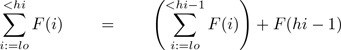

如果我的写法正确，那么我们预期这两个函数返回相同的结果。我们来证明这一点。If I wrote them correctly, we expect the two functions to return the same result. Let's prove that to be so.

**lemma** SameSums(lo: **int**, hi: **int**)

**requires** lo <= hi

**ensures** SumUp(lo, hi) == SumDown(lo, hi)

**decreases** hi - lo

{

**if** lo != hi {

PrependSumDown(lo, hi);

}

}

**lemma** PrependSumDown(lo: **int**, hi: **int**)

**requires** lo < hi

**ensures** F(lo) + SumDown(lo + 1, hi) == SumDown(lo, hi)

**decreases** hi - lo

{

}

这两个引理中对归纳假设的所有运用都由 Dafny 的自动归纳处理，不过，要让它顺利完成，你必须提供恰当的 **decreases** 子句（与所涉及函数的子句相同）。如果忘记这样做，就会收到验证器无法证明引理的错误。随后，在手动证明中尝试递归调用引理时，你就会发现需要这些 **decreases** 子句。All appeals to the induction hypotheses of these two lemmas are handled by Dafny's automatic induction, but for this to work out, you do need to supply the appropriate **decreases** clauses (which are the same as for the functions involved). If you forgot to do so, you would get an error that the verifier can't prove the lemmas. You would then discover the need for these **decreases** clauses when you tried to call the lemmas recursively in your manual proofs.

## 练习12.6。Exercise 12.6.

函数 SumUp 和 SumDown 的默认 **decreases** 子句是什么？解释为什么它们不能用于证明终止性。What are the default **decreases** clauses for functions SumUp and SumDown? Explain why they do not work to prove termination.

## 练习12.7。Exercise 12.7.

为两个引理都添加 {:induction **false**} 标注，并补全证明。Mark both of the lemmas with {:induction **false**} and fill in the proofs.

## 练习12.8。Exercise 12.8.

不依赖自动归纳，证明Without relying on automatic induction, prove

**lemma** AppendSumUp(lo: **int**, hi: **int**)

**requires** lo < hi

**ensures** SumUp(lo, hi - 1) + F(hi - 1) == SumUp(lo, hi)

### 12.3.1. 通过迭代求和12.3.1. Computing sums by iteration

编写循环来求和也有两种方式。假设 lo <= hi，下面是一种循环索引递增的循环实现。我将这个循环称为 LoopUp。There are also two ways to write a loop to compute the sum. Assuming lo <= hi, here is a loop implementation where the loop index increases. I will refer to this loop as LoopUp.

s, i := 0, lo;

**while** i != hi

**invariant** lo <= i <= hi

{

s := s + F(i);

i := i + 1;

}

下面是一种循环索引递减的循环实现。我将这个循环称为 LoopDown。And here is a loop implementation where the loop index decreases. I will refer to this loop as LoopDown.

s, i := 0, hi;

**while** i != lo

**invariant** lo <= i <= hi

{

i := i - 1;

s := s + F(i);

}

如果要证明这些循环将总和计算到 s 中，那么每个循环还都需要一个关于 s 的循环不变式。If we want to prove that these loops compute the sum into s, then, for each loop, we'll also need a loop invariant about s.

### 12.3.2. 验证求和12.3.2. Verifying the sum

我们重点看 LoopUp。使用将常量（hi）替换为变量（i）的技巧，关于 s 的循环不变式的一个合理候选是Let's focus on LoopUp. Using the technique of replacing a constant (hi) with a variable (i), a reasonable candidate for its loop invariant about s is

**invariant** s == SumUp(lo, i)

由于我们将 i 初始化为 lo，进入循环时这个不变式成立。它使我们能够在循环后得出 s == SumUp(lo, hi)，因为此时 i 为 hi。但验证器报告说，循环体未能维持不变式。 为了找出原因，我们写出一些注释，从循环体末尾所需的循环不变式反向推导，遇到赋值语句时执行代换：This loop invariant is established on entry to the loop, since we initialized i to lo. It lets us conclude s == SumUp(lo, hi) after the loop, since i is hi there. But the verifier complains that the invariant is not maintained by the loop body. To figure out why, let's write out some annotations, working backward from the desired loop invariant at the end of the loop body and using substitutions as we encounter assignments:

{{ s == SumpUp(lo, i) }}

{{ s + F(i) == SumpUp(lo, i + 1) }}

s := s + F(i);

{{ s == SumpUp(lo, i + 1) }}

i := i + 1;

{{ s == SumpUp(lo, i) }}

我们的证明义务是证明第一条注释蕴含第二条。现在可以看出问题所在：SumUp(lo, i) 是用 SumUp(lo + 1, i) 定义的，但我们需要得出关于 SumUp(lo, i + 1) 的结论。因此，求和的方向不对。Our proof obligation is to show that the first annotation implies the second. We can now see the problem: SumUp(lo, i) is defined in terms SumUp(lo + 1, i), but we need to conclude something about SumUp(lo, i + 1). So, the summation goes the wrong way.

有三种方法可以解决这个问题。There are three ways to fix this problem.

一种解决方法是使用一个引理，告诉我们增大传给 SumUp 的上界会发生什么。在进入循环体时调用One way to fix the problem is to use a lemma that tells us what happens when you increase the upper bound passed to SumUp. By calling

AppendSumUp(lo, i + 1);

（见练习12.8），或者在递增 i 之后调用 AppendSumUp(lo, i)，验证就能通过。类似地，对于 LoopDown，需要在循环体末尾调用 PrependSumDown(i, hi)（如果在递减 i 之前调用，则使用 PrependSumDown(i - 1, hi)）。(see Exercise 12.8) on entry to the loop body (or calling AppendSumUp(lo, i) after the increment of i), the verification goes through. Analogously, for LoopDown, you need to call PrependSumDown(i, hi) at the end of the loop body (or PrependSumDown(i - 1, hi) if you call it before the decrement of i).

第二种解决方法是改变循环不变式。不用 SumUp 表述，而改用 SumDown，因为 SumDown 的定义直接说明了增大上界时会发生什么。A second way to fix the problem is to change the loop invariant. Instead of writing it in terms of SumUp, we can write it in terms of SumDown, since the definition of SumDown directly says what happens when you increase the upper bound.

**invariant** s == SumDown(lo, i)

你可以看出，LoopUp 的不变式中需要 SumDown。也就是说，当你向上迭代时，所需函数的递归方向是向下的。反过来，要证明 LoopDown，所需的不变式为What you can see is that LoopUp needs SumDown in its invariant. That is, when you iterate up, the function you need recurses downward. Conversely, to prove LoopDown, the invariant you need is

**invariant** s == SumUp(i, hi)

这一点值得记住。但还有一种可能的解决方法，它让你可以将 SumUp 与 LoopUp 搭配使用，将 SumDown 与 LoopDown 搭配使用。This is a good thing to remember. But there's one more possible fix, and it lets you use SumUp with LoopUp and use SumDown with LoopDown.

第三种解决方法是将描述已完成工作的不变式，替换为描述尚待完成工作的不变式，就像*尚待完成的工作*这一循环设计技巧12.1中提到的那样。对于 LoopUp，不变式就变为The third way to fix the problem is to replace the what-has-been-done invariant with a what's-yet-to-be-done invariant, as I mentioned in the *yet to be done* Loop Design Technique 12.1. For LoopUp, the invariant then becomes

**invariant** s + SumUp(i, hi) == SumUp(lo, hi)

描述已完成工作的不变式常见得多，因此你可能没有想到这种表述方式。但仔细看，它相当自然。一次循环迭代所做的，实质上就是将 F(i) 这一项从 Sum(i, hi) 移到 s 中。What-has-been-done invariants are far more common, so you may not have thought about this possible formulation. But when you look at it, it's quite natural. Essentially what one loop iteration does is move the term F(i) from Sum(i, hi) into s.

## 练习12.9。Exercise 12.9.

证明以下引理。Prove the following lemma.

**lemma** SumRanges(lo: **int**, mid: **int**, hi: **int**)

**requires** lo <= mid <= hi

**ensures** SumUp(lo, mid) + SumUp(mid, hi) == SumUp(lo, hi)

### 12.3.3. 程序汇总12.3.3. Summary of programs

为便于并排比较，下面列出求和方法的不同版本：For side-by-side comparisons, here are the different versions of the sum method:

[output not shown]

在这些程序中，你或许还注意到一点：循环索引向上变化的循环，在循环体末尾、循环体其余部分使用完索引之后，才递增循环索引。这称为*后置递增*。循环索引向下变化的循环，则在循环体开头、其余部分使用索引之前，就递减循环索引。这称为*前置递减*。采用后置递增和前置递减是典型做法。One additional point you may notice in these programs is that loops where the loop index goes upward perform the increment of the loop index at the end of the loop body, after the rest of the body uses it. This is called *post-incrementing*. Loops where the loop index goes downward perform the decrement of the loop index at the beginning of the loop body, before the rest of the body uses it. This is called *pre-decrementing*. It is typical to do post-increments and pre-decrements.

## 12.4. 小结12.4. Summary

我们经常编写规约由函数式定义给出的命令式程序。这时，需要确保递归的方向与迭代的方式相匹配。任何不一致都可以通过证明恰当的引理来解决，不过，也可能找到一种循环不变式的表述，使它同时符合递归定义和循环实现。We frequently write imperative programs whose specifications are given by functional definitions. When we do, we need to make sure the direction of recursion matches up with the way we do iterations. Any discrepancies can be solved by proving appropriate lemmas, but it may also be possible to phrase loop invariants in a way that fits both the recursive definitions and the loop implementations.

比较方向不同的循环时，我们看到：向上循环对循环索引采用后置递增，向下循环对循环索引采用前置递减。While comparing loops that go in different directions, we saw the use of post-increments of the loop index in upward loops and pre-decrements of the loop index in downward loops.

在编写这些程序的过程中，我还介绍了另外两项循环设计技巧。这些技巧对于熟练掌握程序证明至关重要。Among the programs we wrote, I also presented two more loop design techniques. These techniques are essential for mastery of program proofs.

## 注释Notes

本章展示了描述已完成工作的不变式（这是最常见的）以及描述尚待完成工作的不变式。为了更直接地便于从尚待完成工作的角度进行推理，可以使用带规约的可调用块语句。正如 Eric Hehner 所展示的，这种*带规约的块*有时能自然地替代 **while** 语句 [62]。In this chapter, I showed both what-has-been-done invariants (which are most common) and what's-yet-to-be-done invariants. To more directly facilitate reasoning in terms of what has yet to be done, one can use invocable block statements with specifications. As Eric Hehner shows, such *specified blocks* sometimes provide a natural alternative to **while** statements [62].

# 第13章 数组与搜索Chapter 13 Arrays and Searching

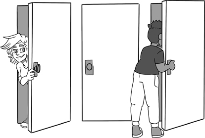

*数组*是一种简单的可变数据结构。它的元素通过称为*索引*的数值访问，这些数值在运行时计算。本章研究如何编写和验证使用数组的程序。这将引领我们接触大量实用、有趣、有时又颇为微妙的算法。An *array* is a simple mutable data structure. Its elements are accessed by numeric values, called *indices*, that are computed at run time. In this chapter, we look at how to write and verify programs that use arrays. This ushers us into a wealth of useful, interesting, and sometimes subtle algorithms.

## 13.0. 关于数组13.0. About Arrays

我假设你以前见过并使用过数组。不过，为了确保我们讨论的是同一种数组，还是先回顾一下要点。I assume you have seen and used arrays before. But just to make sure we're talking about the same kinds of arrays, let's go over the essentials.

### 13.0.0. 数组分配与长度13.0.0. Array allocation and length

数组存储固定数量的元素，通过从 0 开始的连续索引来寻址。数组的*长度*在分配数组时确定。下面的程序语句分配一个长度为 100 的数组，并将局部变量 a 设为引用该数组。An array stores a fixed number of elements, addressable by consecutive indices starting from 0. The *length* of an array is determined when the array is allocated. The following program statement allocates an array of length 100 and sets local variable a to reference this array.

**var** a := **new int**[100];

下图说明变量 a，它的值是对所分配数组的引用：Here's a diagram that illustrates variable a, whose value is a reference to the allocated array:

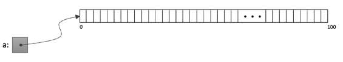

可以通过数组的 Length 成员取得 a 的长度。例如，在上述赋值之后，可以证明We can obtain the length of a by the array's Length member. For example, after the assignment above, we can prove

**assert** a.Length == 100;

这 100 个元素中每个元素的类型都是 **int**。a 的类型为 **array**<**int**>，与 a 的长度无关。这意味着可以更新 a，使它引用另一个 **int** 数组，即使那个数组的长度不同。例如，The type of each of the 100 elements is **int**. The type of a is **array**<**int**>, which is independent of the length of a. This means we can update a to reference another **int**-array, even if that array has a different length. For example,

a := **new int**[20];

会分配一个长度为 20 的数组，并将上文的 a 设为引用它。新情况如下图所示：allocates an array of length 20 and sets a (from above) to reference it. The new situation is illustrated as follows:

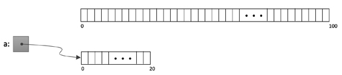

### 13.0.1. 数组元素13.0.1. Array elements

数组 a 中索引为 i 的元素通过表达式 a[i] 访问。这里的证明义务是 i 必须是 a 的有效索引，即必须证明The element at index i of an array a is accessed by the expression a[i]. It is a proof obligation that i be a proper index of a, that is, we have to prove

0 <= i < a.Length

这样的数组访问可以用作赋值语句的左侧。例如，Such an array access can be used as the left-hand side of an assignment. For example,

a[9] := a[9] + 5;

将 a 的第 9 号元素增加 5。increments element 9 of a by 5.

更新一个数组元素不会影响数组的其他元素。例如，下面程序中的断言可以得到证明：The update of one array element has no effect on the other elements of the array. For example, the assertion in the following program is provable:

a[6] := 2;

a[7] := 3;

**assert** a[6] == 2 && a[7] == 3;

当然，如果两个整数表达式求得相同的值，那么用它们作为数组索引将访问同一个数组元素。例如，Of course, if two integer expressions evaluate to the same value, then using those expressions when indexing an array will access the same array element. For example,

**method** TestArrayElements(j: **nat**, k: **nat**)

**requires** j < 10 && k < 10

{

**var** a := **new int**[10];

a[j] := 60;

a[k] := 65;

**if** j == k {

**assert** a[j] == 65;

} **else** {

**assert** a[j] == 60;

}

}

这个方法说明，当 j == k 时，第二次赋值会覆盖第一次；而如果 j != k，则不会影响第一次赋值。This method illustrates that the second assignment overwrites the first when j == k, and that it has no effect on the first if j != k.

### 13.0.2. 数组是引用13.0.2. Arrays are references

Dafny 中数组的一个重要特点是：它们是对其元素的*引用*。因此，复制数组时，复制的是数组引用，而不是数组元素。下面的程序片段说明了这一点：An important aspect of arrays in Dafny is that they are *references* to their elements. Consequently, when you copy an array, you're copying the array reference, not the array elements. This program fragment illustrates:

**var** a := **new string**[20];

a[7] := "hello";

**var** b := a;

**assert** b[7] == "hello";

b[7] := "hi";

a[8] := "greetings";

**assert** a[7] == "hi" && b[8] == "greetings";

下图显示该程序片段执行后的情况：The following diagram shows the situation after the program fragment:

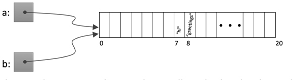

这个例子中只有一个数组。它被分配为长度 20，元素类型为 **string**。局部变量 a 被设为引用该数组，第 7 号元素被设为 "hello"。对 b 的赋值使 b 引用与 a 相同的数组。因此，在此例后续部分中，由于 a 与 b 相等（也就是说，它们是同一个数组引用），使用哪个局部变量访问数组都没有区别。There is only one array in this example. It is allocated to have length 20 and its element type is **string**. Local variable a is set to reference the array, and element 7 is set to "hello". The assignment to b makes b reference the same array as a does. Thus, for the rest of the example, since a and b are equal (that is, they are the same array reference), it doesn't matter which local variable is used to access the array.

继续这个例子，注意 a 和 b 是不同的局部变量。因此，如果将 b 设为引用另一个数组，a 仍然引用原来的数组。Continuing this example, note that a and b are different local variables. Therefore, if b is set to reference a different array, then a still references the previous array.

b := **new string**[8];

b[7] := "long time, no see";

**assert** a[7] == "hi";

**assert** a.Length == 20 && b.Length == 8;

### 13.0.3. 多维数组13.0.3. Multi-dimensional arrays

Dafny 中的数组可以有多个维度。下面的例子分配一个2维数组（通常称为*矩阵*）：An array in Dafny can have more than one dimension. Here's an example that allocates a 2-dimensional array (usually called a *matrix*):

**var** m := **new bool**[3, 10];

m[0, 9] := **true**;

m[1, 8] := **false**;

**assert** m.Length0 == 3 && m.Length1 == 10;

这个矩阵的元素类型为 **bool**，m 的类型为 **array2**<**bool**>。每个维度都有一个长度，可以通过成员 Length0 和 Length1 获得这些长度。The element type of this matrix is **bool**, and the type of m is **array2**<**bool**>. Each dimension has a length, and these lengths are obtained using the members Length0 and Length1.

我将主要使用1维数组。I will mostly use 1-dimensional arrays.

### 13.0.4. 序列13.0.4. Sequences

数组有一个近亲，即*序列*。数组是可变的，并通过引用访问；而序列是不可变的值，就像布尔值、整数和数据类型的值一样。因此，数组类型通常称为*引用类型*，序列类型称为*值类型*。A cousin of arrays are *sequences*. Whereas arrays are mutable and are accessed via references, sequences are immutable values, just like booleans, integers, and datatypes are. For this reason, array types are often called *reference types* and sequence types *value types*.

与数组一样，序列的元素必须具有共同的类型。序列类型构造器写为 **seq**，因此 **seq**<**int**> 表示整数序列，**seq**<**bool**> 表示布尔值序列。The elements of a sequence must have a common type, just as for arrays. The sequence type constructor is written **seq**, so **seq**<**int**> denotes integer sequences and **seq**<**bool**> denotes sequences of booleans.

由于数组是对存储在堆中的元素的引用，因此如上所示，要使用 **new** 创建数组。写出序列值的最简单方法是在方括号中列出其元素。例如，[] 表示空序列，[58] 表示仅含整数元素 58 的单元素序列，而Since an array is a reference to elements stored in the heap, an array is created using **new**, as we saw above. The simplest way to write down a sequence value is to list its elements between square brackets. For example, [] denotes the empty sequence, [58] denotes the singleton sequence with the integer element 58, and

["hey", "hola", "tjena"]

是由三个字符串组成的序列。is a sequence of three strings.

序列索引访问的语法与数组相同。例如，如果 greetings 表示上面的字符串序列，那么 greetings[2] 就是 "tjena"。数组 a 的长度写为 a.Length，但序列 a 的长度写为 |a|。例如，|[]| 为 0，|greetings| 为 3。Indexing into a sequence has the same syntax as for arrays. For example, if greetings denotes the sequence of strings above, then greetings[2] is "tjena". The length of an array a is written a.Length, but the length of a sequence a is written |a|. For example, |[]| is 0 and |greetings| is 3.

可以使用 + 连接序列。下面是一个涉及五边形数的例子：Sequences can be concatenated using +. Here is an example with some pentagonal numbers:

[1, 5, 12] + [22, 35] == [1, 5, 12, 22, 35]

获得序列的另一种方式是取另一个序列的子序列。表达式 a[lo..hi] 表示 a 的一个长度为 hi - lo 的子序列，其获取方法是取 a 的前 hi 个元素，再丢弃其中的前 lo 个元素。该操作要求Another way to obtain a sequence is as a subsequence of another sequence. The expression a[lo..hi] denotes the subsequence of a of length hi - lo obtained by taking the first hi elements of a and then dropping the first lo elements thereof. The operation requires

0 <= lo <= hi <= |a|

如果下界为 0，就可以省略；如果上界为序列长度，也可以省略。下面给出一些例子，其中用 p 表示上面由五个五边形数组成的序列：If the lower bound is 0, it can be omitted, and if the upper bound is the length of the sequence, it can be omitted. Here are some examples, where I'm using p to denote the sequence of five pentagonal numbers above:

p[2..4] == [12, 22]

p[..2] == [1, 5]

p[2..] == [12, 22, 35]

greetings[..1] == ["hey"]

greetings[1..2] == ["hola"]

对 p 应用 p[2..] 这样的操作，读作“丢弃 2 个”，而操作 p[..2] 读作“取 2 个”。An operation like p[2..] applied to p is pronounced “drop 2” and the operation p[..2] is pronounced “take 2”.

也可以从一段数组元素获得序列，所用语法与对子序列执行取和丢弃操作的语法相同。要获得包含数组 a 全部元素的序列，可以同时省略上下界，写成 a[..]。注意，序列值由数组当前的元素创建，不受数组未来变化的影响。例如，下面代码片段中的断言全部成立：It is also possible to obtain a sequence from a stretch of array elements. This uses the same syntax as the take and drop operations for subsequences. To obtain a sequence of all the elements of an array a, you can drop both the lower and upper bounds, writing a[..]. Note that the sequence value is created from the current array elements and is not sensitive to future changes of the array. For example, the assertions in the following code snippet all hold:

**var** a := **new int**[3];

a[0], a[1], a[2] := 6, 28, 496;

**assert** a[..2] == [6, 28] && a[1..] == [28, 496];

**var** s := a[..];

**assert** s == [6, 28, 496];

a[0] := 8128;

**assert** s[0] == 6 && a[0] == 8128;

下图显示该代码片段的最终状态。注意，a 包含对数组的引用，而 s 包含一个序列值。The following diagram shows the final state of the code snippet. Note that a contains a reference to an array, whereas s contains a sequence value.

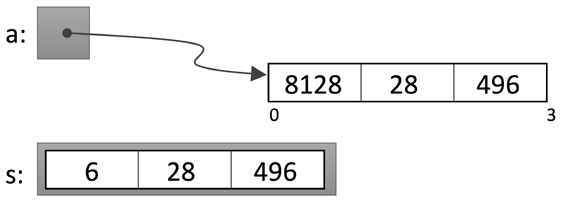

关于数组和序列的背景知识就介绍到这里。该来看一些使用它们的程序了。Enough background on arrays and sequences. It's time for some programs that use them.

## 13.1. 线性搜索13.1. Linear Search

我们考虑一个在数组中查找元素的方法。为使这个方法适用于各种搜索应用，我们用谓词 P 将它参数化，使方法查找满足 P 的数组元素。因此，方法的类型签名为Let's consider a method for finding an element in an array. To make the method usable for various search applications, we'll parameterize it with a predicate P and write the method to look for an array element that satisfies P. The type signature of the method is thus

**method** LinearSearch<T>(a: **array**<T>, P: T -> **bool**) **returns** (n: **int**)

该方法接收类型参数 T，表示数组的元素类型。从 P 的类型可以看出，它接收一个 T 类型的参数并返回一个布尔值。方法有一个输出参数 n，我们用它返回搜索结果。The method takes a type parameter T, which denotes the element type of the array. We can tell from the type of P that it takes an argument of type T and returns a boolean. The method has an out-parameter n, which we'll use to return the findings or our search.

此前我还没有讨论过将函数用作值。这里也不打算多说，只指出：如果声明了一个函数，就可以将该函数的名称用作一等值。例如，假设你声明了I haven't talked about using functions as values before. I won't say much here, either, other than to point out that if you declare a function, then you can use the name of that function as a first-class value. For example, suppose you declare

**predicate** NearPi(r: **real**) {

3.14 <= r <= 3.15

}

而 rls 是 **array**<**real**> 类型的变量，那么可以按如下方式调用上述方法：and rls is a variable of type **array**<**real**>, then you can call the method above as follows:

**var** n := LinearSearch(rls, NearPi);

注意，由于参数 P 不是幽灵参数，在 LinearSearch 调用处传入的值也必须不是幽灵值，因此将 NearPi 声明为会被编译的谓词。Note that, since parameter P is non-ghost, the value passed in at the call site of LinearSearch must also be non-ghost, so NearPi is declared to be a compiled predicate.

我们将考虑的 LinearSearch 的方法实现会逐一遍历数组元素。这种算法称为线性搜索。The method implementations we'll consider for LinearSearch go through the array elements one by one. The name for such an algorithm is Linear Search.

我将介绍规约及相应程序的几种变体，借此引入编写数组程序规约的一种常见结构：逻辑量词。I will go through several variations of the specification and corresponding program, which will let me introduce a common construct for writing specifications of array programs: logical quantifiers.

### 13.1.0. 一个简单规约13.1.0. A simple specification

作为热身，我们编写一个简单规约，返回闭区间 0 <= n <= a.Length 内的 n，其中严格小于 a.Length 的值表示数组元素满足 P 的某个索引。As a warm-up, let's write a simple specification that returns n in the inclusive range 0 <= n <= a.Length, where a value strictly less than a.Length indicates an index where the array element satisfies P.

**method** LinearSearch0<T>(a: **array**<T>, P: T -> **bool**) **returns** (n: **int**)

**ensures** 0 <= n <= a.Length

**ensures** n == a.Length || P(a[n])

在实现中，我们将输出参数 n 用作循环索引。循环规约如下：For our implementation, we will use the out-parameter n as our loop index. Here is the loop specification:

{

n := 0;

**while** n != a.Length

**invariant** 0 <= n <= a.Length

}

这个循环规约足以建立方法的后置条件，因为循环后可以得出 n == a.Length，这是方法规约所允许的。This loop specification is enough to establish the method postcondition, because we can conclude n == a.Length after the loop, which the method specification allows.

循环体将递增 n，而在此之前，会检查当前数组元素是否满足 P。假如满足，该怎么办呢？此时任务已经完成，我们不想再费心处理循环不变式和其他义务。直截了当地说，我们已经准备好直接退出。可以用 **return** 语句来做到这一点，它会立即终止方法体。在执行 **return** 时，必须立即证明方法的后置条件成立。另一种理解方式是，将 **return** 语句看作跳到方法体的最末尾，此时需要证明方法的后置条件成立；两种理解的结果相同。The loop body is going to increment n, and before doing so, it will check if P holds of the current array element. But suppose it does, what do we do then? Well, our mission is then done, so we'd rather not bother with loop invariants and other obligations. To put it bluntly, we're ready to head straight to the exit. We can do that with a **return** statement, which abruptly terminates the method body. At the time of a **return**, you immediately have to prove that the method postcondition holds. Alternatively, and with the same consequences, you can think of the **return** statement as jumping to the very end of the method body, at which point you need to prove that the method post-condition holds.

因此，LinearSearch0 的完整方法体如下：So, here is the full method body of LinearSearch0:

n := 0;

**while** n != a.Length

**invariant** 0 <= n <= a.Length

{

**if** P(a[n]) {

**return**;

}

n := n + 1;

}

除了用 **return** 跳到方法体末尾，也可以使用 **break** 语句，它会立即终止循环，并紧接着从循环之后继续执行方法体。这在许多程序中都很常见。执行 **break** 时，无须证明循环不变式成立，而且无论当时循环守卫是否成立，都允许执行 **break**。我曾说过，紧接循环之后，你可以依赖不变式和守卫的否定成立；但如果循环使用 **break**，这一点就不成立了。循环体每使用一条 **break**，就会多出一组经过循环体到达循环出口的路径。除了这些差异外，**break** 不会带来问题，验证器完全理解这些额外的循环出口。不过，为使处理方式稍微一致一些，本书将避免使用 **break**。Instead of using a **return** to jump to the end of the method body, you can use a **break** statement, which abruptly terminates the loop, continuing the execution of the method body immediately after the loop. This is common in many programs. You do not need to prove that the loop invariant holds at the time you do a **break**, and you're allowed to do a **break** regardless of if the loop guard holds at that moment. I've told you that you can rely on the invariant and the negation of the guard to hold immediately after the loop, but this is not true if the loop uses a **break**. For every **break** that a loop body uses, there's an additional set of paths through the loop body to its exit. Other than these differences, a **break** poses no problems, and the verifier understands all about the additional loop exits. Nevertheless, to keep things a bit more consistent, I will avoid the use of **break** in this book.

### 13.1.1. 必须为失败提供理由13.1.1. Having to justify defeat

方法 LinearSearch0 的规约允许一种比使用循环还容易的实现：只需将整个方法体改为 n := a.Length。（如果有一个表情符号能表示《小熊维尼》中那段令人失望的长号声，我会把它放在这里。）我们不希望规约允许实现如此轻易地放弃。如果方法返回 a.Length，我们就希望说明 a 中没有满足 P 的元素。为此需要逻辑量词。我将使用*全称量词*，在 Dafny 中写为 **forall**，在逻辑中写为 ∀。它引入一个绑定变量，并说明某个条件对该绑定变量普遍成立，即对它的所有值都成立。The specification of method LinearSearch0 admits an implementation that is even easier than using a loop: just change the entire method body into n := a.Length. (If there was an emoji for the Winnie the Pooh trombone fanfare of disappointment, I would insert it here.) We don't want our specification to allow an implementation to give up so easily. If the method returns a.Length, then we'd like to say that there is no element in a that satisfies P. Doing so requires a logical quantifier. I'll use a *universal quantifier*, written **forall** in Dafny and ∀ in logic. It introduces a bound variable and says that a condition holds universally for—that is, for all values of—that bound variable.

下面是一个涉及所有整数 x 的量词示例，其中 Fib 是斐波那契函数（3.1节）：Here is an example quantifier that speaks of all integers x, where Fib is the Fibonacci function (Section 3.1):

**forall** x: **int** :: 5 <= x ==> 5 <= Fib(x)

如果量词的*体*，即“::”右侧的表达式，对每个整数 x 都成立，那么这个表达式的值为 **true**；否则为 **false**。This expression has the value **true** if the *body* of the quantifier—that is, the expression to the right of the “::”—holds for every integer x, and the value **false** otherwise.

## 练习13.0。Exercise 13.0.

上面量词示例的值是什么，**false** 还是 **true**？What is the value, **false** or **true**, of the example quantifier above?

与局部变量一样，如果类型可以推断，就可以省略类型“: **int**”。As for local variables, we can leave off the type “: **int**” if the type can be inferred.

改进后的线性搜索方法规约如下：Here is our improved specification for the linear-search method:

**method** LinearSearch1<T>(a: **array**<T>, P: T -> **bool**) **returns** (n: **int**)

**ensures** 0 <= n <= a.Length

**ensures** n == a.Length || P(a[n])

**ensures** n == a.Length ==>

**forall** i :: 0 <= i < a.Length ==> !P(a[i])

它的意思是，如果 n 返回为 a.Length，那么对于范围 0 <= i < a.Length 内的每个 i，!P(a[i]) 都成立。这看起来很不错，因为当*确实存在*满足 P 的元素时，它禁止实现返回 a.Length。This says that, in the event that n is returned as a.Length, then !P(a[i]) holds for every i in the range 0 <= i < a.Length. This looks pretty good, because it prevents the implementation from returning a.Length when there *is* an element satisfying P.

方法规约改进后，循环不变式应是什么样的呢？我们应用*用变量替换常量*这一循环设计技巧12.0。循环之后，希望成立的条件是With the improved method specification, what will our loop invariant look like? Let's apply the *replace constant by variable* Loop Design Technique 12.0. After the loop, we want the condition

**forall** i :: 0 <= i < a.Length ==> !P(a[i])

我们已经有变量 n，它在循环之后会等于常量 a.Length，因此用变量 n 替换该常量，就得到如下循环不变式：We already have a variable n that will equal the constant a.Length after the loop, so by replacing that constant by the variable n, we arrive at the following loop invariant:

**invariant forall** i :: 0 <= i < n ==> !P(a[i])

循环实现与 LinearSearch0 完全相同，不过我们仔细看看它为什么有效。在循环体对 n 的递增操作周围写出注释，得到：Our loop implementation will be exactly the same as in LinearSearch0, but let's take a detailed look at why it works. Writing annotations around the loop body's increment of n, we get:

{{ **forall** i :: 0 <= i < n + 1 ==> !P(a[i]) }}

n := n + 1

{{ **forall** i :: 0 <= i < n ==> !P(a[i]) }}

0 <= i < n + 1

=

0 <= i < n || i == n

第二个等式是量词的*范围拆分*（参见B.7节），其一般形式为The second equality is a quantifier *Range Split* (cf. Section B.7), which has the general form

**forall** x :: A || B ==> C

=

(**forall** x :: A ==> C) && (**forall** x :: B ==> C)

应用范围拆分，分别将 x、A、B、C 取为 i、0 <= i < n、i == n、!P(a[i])，得到：We apply Range Split with x and A and B and C as i and 0 <= i < n and i == n and !P(a[i]), respectively, which gives us:

**forall** i :: 0 <= i < n || i == n ==> !P(a[i])

=

(**forall** i :: 0 <= i < n ==> !P(a[i])) &&

(**forall** i :: i == n ==> !P(a[i]))

第三个等式称为*单点规则*（参见B.7节），它提供了一种消去量词的方法。其一般形式为The third equality is known as the *One-Point Rule* (cf. Section B.7) and gives us a way to eliminate a quantifier. Its general form is

**forall** x :: x == E ==> A

=

A**[**x := E**]**

其中，E 是不含 x 的表达式。最后一行使用代换（我在2.3节首次介绍过，也可参见B.6节），将 A 中每一处 x 替换为 E。在这里，我们应用单点规则，分别将 x、E、A 取为 i、n、!P(a[i])：where E is an expression that does not mention x. The last line uses a substitution (which I first introduced in Section 2.3, but see also Section B.6) that replaces every occurrence of x in A by E. In our situation, we apply the One-Point Rule with x and E and A as i and n and !P(a[i]), respectively:

**forall** i :: i == n ==> !P(a[i])

=

!P(a[n])

回到 n := n + 1 周围的注释，上面三个等式使我们能够将递增 n 之前的条件写为：Going back to the annotations around n := n + 1, the three equalities above allow us to write the condition before the increment of n as follows:

{{ (**forall** i :: 0 <= i < n ==> !P(a[i])) && !P(a[n]) }}

{{ **forall** i :: 0 <= i < n + 1 ==> !P(a[i]) }}

n := n + 1

{{ **forall** i :: 0 <= i < n ==> !P(a[i]) }}

这是个好消息。第一个合取项由进入循环体时的循环不变式保证，第二个合取项在 **if** 语句后成立（因为如果 P(a[n]) 确实成立，then 分支就会使用 **return** 跳到方法末尾）。This is good news. The first of the conjuncts holds on account of the loop invariant on entry to the loop body, and the second conjunct holds after the **if** statement (because the then branch uses a **return** to jump to the end of the method if P(a[n]) does hold).

这就证明了 LinearSearch1 的正确性。That proves the correctness of LinearSearch1.

### 13.1.2. 查找第一个元素13.1.2. Finding the first element

即使在找到元素的情况下，也很容易让方法规约更精确：我们可以承诺返回满足 P 的元素第一次出现的位置。为此，说明数组的前 n 个元素中没有满足 P 的元素。在 LinearSearch1 中添加的后置条件是这个条件的较弱形式，因此我们用一个新子句替换那个 **ensures** 子句：We can easily be more precise in our method specification even in the case where an element is found: we can promise to return the first occurrence of an element satisfying P. To that end, we'll say that there's no element satisfying P among the first n elements of the array. The postcondition we added in LinearSearch1 was a weaker form of this, so we replace that **ensures** clause with a new one:

**method** LinearSearch2<T>(a: **array**<T>, P: T -> **bool**) **returns** (n: **int**)

**ensures** 0 <= n <= a.Length

**ensures** n == a.Length || P(a[n])

**ensures forall** i :: 0 <= i < n ==> !P(a[i])

LinearSearch1 的循环规约和循环体也适用于新方法。The loop specification and body from LinearSearch1 also work for our new method.

### 13.1.3. 已知目标存在13.1.3. Knowing it's there

我们再看一种线性搜索的变体，其中已知搜索目标存在。这意味着可以简化后置条件，去掉 n == a.Length 这一特殊情况。为了在规约中写出这个新假设，我们使用前置条件。最直接的写法是使用*存在量词*，在 Dafny 中写为 **exists**，在逻辑中写为 ∃。Let's do one more variant of Linear Search, one where we're given that the search item exists. This means we can simplify the postcondition to remove the special case n == a.Length. To specify this new assumption, we use a precondition. The most straight-forward way to write the condition is to use an *existential quantifier*, written **exists** in Dafny and ∃ in logic.

下面是一个对整数作存在量化的例子：Here is an example that existentially quantifies over the integers:

**exists** x :: 0 <= x && Fib(x) == 143

如果存在某个整数使量词体成立，则此表达式的值为 **true**；否则为 **false**。This expression has the value **true** if there is some integer for which the body holds, and the value **false** otherwise.

## 练习13.1。Exercise 13.1.

上面量词示例的值是什么，**false** 还是 **true**？What is the value, **false** or **true**, of the example quantifier above?

在前置条件中加入存在量词后，新的线性搜索规约如下：With an existential quantifier in its precondition, our new linear-search specification looks like this:

**method** LinearSearch3<T>(a: **array**<T>, P: T -> **bool**) **returns** (n: **int**)

**requires exists** i :: 0 <= i < a.Length && P(a[i])

**ensures** 0 <= n < a.Length && P(a[n])

前置条件说，存在一个索引 i，使 P(a[i]) 成立；后置条件说，n 是使 P(a[n]) 成立的一个索引。The precondition says there exists an index i such P(a[i]) holds, and the postcondition says that n is an index such that P(a[n]) holds.

全称量词与存在量词的表述有一个重要区别：全称量词的体的主要联结词是蕴含，而存在量词的是合取。例如，要说明 P(a[i]) 对*所有*索引成立，我们写An important difference in how we formulate universal and existential quantifiers is that the main connective of the body of universal quantifiers is an implication, whereas it is a conjunction for existential quantifiers. For example, to say that P(a[i]) holds for *all* indices, we write

**forall** i :: 0 <= i < a.Length ==> P(a[i])

而要说明它对*某个*索引成立，则写whereas to say that it holds for *some* index, we write

**exists** i :: 0 <= i < a.Length && P(a[i])

如果将 ==> 改为 &&，那么 **forall** 表达式就会说，所有整数都在 0 到 a.Length 的范围内，这并不成立（例如 -1 就不在其中）。因此，**forall** 表达式的值会是 **false**。反过来，如果将 && 改为 ==>，那么 **exists** 表达式就会说，存在一个整数 i，*如果*它在 0 到 a.Length 的范围内，*那么*后面的条件成立。对于任何不在该范围内的整数，这都显然成立，而这样的整数有很多（例如 -1 就是一个）。因此，**exists** 表达式的值会是 **true**。If we changed the ==> to an &&, then the **forall** expression would say that all integers are in the range from 0 to a.Length, which isn't true (for example, -1 isn't). Thus, the **forall** expression would have the value **false**. Conversely, if we changed the && to an ==>, then the **exists** expression would say there's an integer i such that *if* the integer is in the range from 0 to a.Length, *then* yada yada. This is trivially true for any integer not in that range, of which there are plenty (for example, -1 is one). Thus, the **exists** expression would have the value **true**.

你可能感到惊讶：LinearSearch1 和 LinearSearch2 的方法实现及循环不变式同样适用于 LinearSearch3。为什么呢？在 **return** 语句处满足后置条件并不奇怪。令人意外的可能是循环之后的情况：守卫的否定告诉我们 n 为 a.Length，但新规约不允许返回它。循环之后，我们还知道不变式，因此可以证明以下条件成立：You may be surprised that the same method implementation and loop invariant as for LinearSearch1 and LinearSearch2 also work for LinearSearch3. Why is that? Well, it's no surprise that the postcondition is met at the **return** statement. What may be surprising is what happens after the loop, where the negation of the guard tells us that n is a.Length, which our new specification does not allow us to return. After the loop, we also know the invariant, so we can prove the following condition to hold:

**forall** i :: 0 <= i < a.Length ==> !P(a[i])

下面是另一个有用的性质，称为*量词的德摩根律*（另见B.8节）：Here's another useful property, known as *De Morgan's Law for Quantifiers* (see also Section B.8):

(**forall** x :: !R) == !(**exists** x :: R)

根据它以及布尔逻辑的其他性质，得到：From it and other properties of Boolean logic, we get:

**forall** x :: A ==> B

=

**forall** x :: !A || B

= { *De Morgan's Law* }

**forall** x :: !(A && !B)

= { *De Morgan's Law for Quantifiers* }

!**exists** x :: A && !B

分别将 x、A、B 取为 i、0 <= i < a.Length、P(a[i])，于是有Using x and A and B as i and 0 <= i < a.Length and P(a[i]), we thus have

**forall** i :: 0 <= i < a.Length ==> !P(a[i])

=

!**exists** i :: 0 <= i < a.Length && P(a[i])

其中，第一行是由不变式和守卫的否定得到的条件，第二个表达式则是前置条件的否定。换言之，循环之后，我们能够推出前置条件的否定。这只能说明一件事——控制流永远不会到达这里！where the first line is what we get from the invariant and negation of the guard, and the second expression is the negation of the precondition. In other words, after the loop, we are able to derive a condition that is the negation of the precondition. This can only mean one thing—control never reaches this point!

### 13.1.4. 说明搜索位置的不变式13.1.4. An invariant that says where to look

LinearSearch3 的循环不变式还有一种不同而有趣的写法。在每次迭代开始时，可以说，我们要找的元素位于某个不小于 n 的索引处。There is a different and interesting way to write the loop invariant for LinearSearch3. At the top of every iteration, we can say that the element we're looking for is at some index n or higher.

**exists** i :: n <= i < a.Length && P(a[i])

从这个不变式出发，越过 n 的更新反向推导，得到以下注释：Working backward from this invariant across the update of n, we get the following annotations:

{{ !P(a[n]) && **exists** i :: n <= i < a.Length && P(a[i]) }}

// Range Split and One-Point Rule

{{ !P(a[n]) && (P(a[n]) || **exists** i :: n + 1 <= i < a.Length && P(a[i])) }}

// logic

{{ **exists** i :: n + 1 <= i < a.Length && P(a[i]) }}

n := n + 1

{{ **exists** i :: n <= i < a.Length && P(a[i]) }}

第一个合取项成立，是因为 then 分支执行 **return**；第二个合取项成立，是因为进入循环时不变式成立。因此，上面的循环维持这个不变式。The first conjunct holds on account of that the then branch does a **return**, and the second conjunct holds on behalf of the invariant on entry to the loop. So, the loop from above maintains this invariant.

还可以做两项简化。首先，存在量词蕴含 n < a.Length，因为它说 i 位于两者之间。这意味着可以加强描述 n 范围的不变式：We can perform two more simplifications. First, the existential quantifier implies n < a.Length, since it says that i lies in between. This means we can strengthen the invariant that mentions the range of n:

0 <= n < a.Length

循环守卫总是在循环不变式成立的状态下求值。在 n 的这个范围内，条件 n != a.Length 可以简化为 **true**。不过，这样一来，Dafny 那套简单得近乎笨拙的循环默认 **decreases** 子句生成方案（见11.2.1节）就得不出任何结果，因此需要自行提供一个子句。The loop guard is always evaluated in a state where the loop invariant holds. Under this range of n, the condition n != a.Length can be simplified to **true**. However, if we do, then Dafny's foolishly simple scheme for a default **decreases** clause of the loop (see Section 11.2.1) doesn't come up with anything, so we'll need to supply one ourselves.

LinearSearch3 的最终实现如下：Here is our final implementation of LinearSearch3:

n := 0;

**while true**

**invariant** 0 <= n < a.Length

**invariant exists** i :: n <= i < a.Length && P(a[i])

**decreases** a.Length - n

{

**if** P(a[n]) {

**return**;

}

n := n + 1;

}

这个循环不变式的模式是用变量替换常量的一种变体，不过替换发生在假设中，而不是证明目标中：The pattern in this loop invariant is a variation of replacing a constant by a variable, but the replacement is in the assumption, not in the proof goal:

## **循环设计技巧13.0。**（在前置条件中用变量替换常量）**Loop design technique 13.0.** (Replace constant by variable in precondition)

要从针对某个常量 C、形式为 …C… 的前置条件建立后置条件，可以使用循环不变式 …k…，其中 k 是由循环更新的局部变量，使假设逐渐更加具体。我们可以将其称为*在前置条件中用变量替换常量*。To establish a postcondition from a precondition of the form …C… for some constant C, use a loop invariant …k… where k is a local variable updated by the loop to gradually make the assumption more specific. We may call this *replace constant by a variable in the precondition*.

### 13.1.5. 量词性质总结13.1.5. Summary of quantifier properties

在讨论线性搜索的这一小节中，我们遇到了量词的几个有用性质。下面以不同形式汇总这些性质：In this subsection on Linear Search, we came across several useful properties of quantifiers. Here is a summary of those properties in various forms:

**范围拆分：****Range Split:**

- (**forall** x :: A || B ==> C) <==>  
  (**forall** x :: A ==> C) && (**forall** x :: B ==> C)
- (exists x :: (A || B) && C) <==>  
  (**exists** x :: A && C) || (**exists** x :: B && C)

**单点规则：****One-Point Rule:**

- (**forall** x :: x == E ==> A) <==> A**[**x := E**]**
- (**exists** x :: x == E && A) <==> A**[**x := E**]**

**量词的德摩根律：****De Morgan's Law for Quantifiers:**

- (**forall** x :: A ==> B) <==> !(exists x :: A && !B)
- !(forall x :: A ==> !B) <==> (exists x :: A && B)

附录B还包含量词的其他性质。Appendix B contains additional properties of quantifiers.

## 练习13.2。Exercise 13.2.

为一个线性搜索方法编写规约：它始终返回严格小于 a.Length 的值，并使用负值（而不是 a.Length）表示没有元素满足 P。Write a linear-search specification for a method that always returns a value strictly less than a.Length and uses a negative value (instead of a.Length) to signal that no element satisfies P.

## 13.2. 二分搜索13.2. Binary Search

本节将编写计算机科学中的另一个基础算法：二分搜索。其思路是，如果输入已排序，那么每次循环迭代都可以将搜索空间减半。在这里，我们使用整数数组，搜索给定的键值。通过这个程序，我们将进一步练习*用变量替换常量*这一循环设计技巧12.0。In this section, we'll write another staple from the computer-science pantry, Binary Search. The idea is that if the input is sorted, then we can halve the search space with each iteration of the loop. I'll use an integer array and we'll search for a given key. For this program, we'll get more practice with the *replace constant by variable* Loop Design Technique 12.0.

### 13.2.0. 规定有序性13.2.0. Specifying sortedness

首先要解决的问题是，如何在规约中说明输入已排序。答案如下：We start with the question of how to specify that the input is sorted. Here is the answer:

**forall** i, j :: 0 <= i < j < a.Length ==> a[i] <= a[j]

它的意思是，如果取数组的两个索引 i 和 j，其中 i 在 j 的“左边”，那么这两个索引处的元素具有正确的顺序。（将 i < j 写成 i <= j 也完全可以。）It says that if you take two indices into the array, i and j where i is “to the left” of j, then the elements at those two indices are ordered properly. (It would also be fine to have written i <= j instead of i < j.)

上述写法并非表达数组有序性的唯一方式。另一种方式是嵌套对 i 和 j 的量化，例如What I wrote is not the only way to express that the array is sorted. One alternative way would be to nest the quantifications over i and j. For example, like

**forall** i :: 0 <= i ==>

**forall** j :: i < j < a.Length ==> a[i] <= a[j]

这也可以，但不嵌套的量词通常更容易处理。This works, but unnested quantifiers tend to be easier to work with.

规定有序性的另一种方法是说明相邻元素具有正确的顺序：Another way to specify sortedness is to say that adjacent elements are ordered properly:

**forall** i :: 0 <= i < a.Length - 1 ==> a[i] <= a[i + 1]

这个表达式在逻辑上与前面的表达式等价，但它不能直接表明不相邻的元素也具有正确的顺序。二分搜索会需要这个性质。要得到不相邻元素的这种“传递性”性质，就需要进行归纳证明，这只是徒增工作。因此，不要用这种相邻元素的形式表达有序性。This expression is logically equivalent to the ones above, but it doesn't immediately make it clear that non-adjacent elements are also ordered properly. This is a property we'll need in Binary Search. To get that “transitive” property about non-adjacent elements, we would need to do an inductive proof, which is just extra effort. So, don't express sortedness in this adjacent-elements form.

## 练习13.3。Exercise 13.3.

编写一个量化表达式，说明给定整数数组中的元素严格递增。Write a quantified expression that says the elements in a given integer array are strictly increasing.

## 练习13.4。Exercise 13.4.

证明以下引理，说明可以从相邻元素的性质得到传递性性质。Prove the following lemma, which shows that you can get the transitive property from the adjacent-elements property.

**lemma** SortedTransitive(a: **array**<**int**>, i: **int**, j: **int**)

**requires forall** k :: 0 <= k < a.Length - 1 ==> a[k] <= a[k+1]

**requires** 0 <= i <= j < a.Length

**ensures** a[i] <= a[j]

### 13.2.1. 二分搜索的后置条件13.2.1. Binary Search postcondition

我们可以为二分搜索编写一个类似于线性搜索的后置条件。例如，可以采用 13.1.1节中 LinearSearch1 的后置条件。但方法很容易向调用者提供一些额外信息。我们将返回“最早插入点”：如果键值在数组中存在，就是它最左侧那次出现的索引；如果不在数组中，就是插入它的位置的索引。更准确地说，我们返回其中所有元素都小于所查找键值的最长前缀的长度。换言之，返回一个数 n，使数组的前 n 个元素严格小于键值，而其余元素都至少与键值一样大。We could write a postcondition for Binary Search that is like the one for Linear Search. For example, we could take the postcondition of LinearSearch1 in Section 13.1.1. But it's easy for the method to provide some additional information back to the caller. We'll return the “earliest insertion point”, which means the index of the leftmost occurrence of the key, if it exists in the array, or the index where to insert the key, if it's not in the array. More precisely, we'll return the length of the longest prefix in which everything is less than the key we're looking for. Stated differently, we'll return a number n such that the first n elements of the array are strictly smaller than the key, and the rest of the elements are at least as large as the key.

因此，要编写的二分搜索的规约如下：So, here's the specification of the Binary Search we're going to write:

**method** BinarySearch(a: **array**<**int**>, key: **int**) **returns** (n: **int**)

**requires forall** i, j :: 0 <= i < j < a.Length ==> a[i] <= a[j]

**ensures** 0 <= n <= a.Length

**ensures forall** i :: 0 <= i < n ==> a[i] < key

**ensures forall** i :: n <= i < a.Length ==> key <= a[i]

在开始编写方法实现之前，可以先写一个客户方法，试用“最早插入点”规约。这能让我们对所写规约确实符合意图和预期有一些把握。下面这个方法判断给定键值是否确实位于已排序数组中：Before we launch into writing the implementation of this method, we can try out the “earliest insertion point” specification by writing a client method. This gives us some assurance that the specification we wrote does what we want and expect. Here is a method that determines whether or not a given key is indeed in the sorted array:

**method** Contains(a: **array**<**int**>, key: **int**) **returns** (present: **bool**)

**requires forall** i, j :: 0 <= i < j < a.Length ==> a[i] <= a[j]

**ensures** present == **exists** i :: 0 <= i < a.Length && key == a[i]

{

**var** n := BinarySearch(a, key);

present := n < a.Length && a[n] == key;

}

### 13.2.2. 实现13.2.2. Implementation

二分搜索的主要不变式是：数组中有一个从 lo 到 hi 的子区段，称为“窗口”，我们仍在其中搜索键值。窗口左侧的所有元素都太小，不可能等于键值；我将其称为数组的“过小区”。窗口右侧的所有元素都至少与键值一样大；我将其称为数组的“过大区”。我们不断缩小窗口，直到其大小为 0，此时过小区与过大区相接。每次将窗口大小减半，就能使迭代次数呈对数级。The main invariant of Binary Search is that we have a subsection of the array, a “window”, from lo to hi, where we're still looking for the key. Anything to the left of the window is too small to be the key; I'll call this the “too-small section” of the array. Anything to the right of the window is at least as large as the key; I'll call this the “too-big section” of the array. We'll keep shrinking the window until it has size 0, at which time the too-small section and too-big section meet. We obtain a logarithmic number of iterations by halving the size of the window each time.

下面是循环规约，以及初始和最终赋值。注意，lo 和 hi 代替了后置条件中的 n；也就是说，我们两次应用了*用变量替换常量*这一循环设计技巧12.0。循环之后，lo 与 hi 相等，因此不变式的其余部分以及对 n 的赋值建立了方法的后置条件。Here is our loop specification along with the initial and final assignments. Note that lo and hi take the place of n from the postcondition; that is, we're applying the *replace constant by variable* Loop Design Technique 12.0 twice. After the loop, lo and hi are equal, so the rest of the invariant and the assignment to n establish the method's postcondition.

{

**var** lo, hi := 0, a.Length;

**while** lo < hi

**invariant** 0 <= lo <= hi <= a.Length

**invariant forall** i :: 0 <= i < lo ==> a[i] < key

**invariant forall** i :: hi <= i < a.Length ==> key <= a[i]

n := lo;

}

为实现循环，我们取 lo 与 hi 之间的中点，将该处的元素与键值比较：To implement the loop, we take the midpoint between lo and hi and compare the element at that midpoint with the key:

**var** mid := (lo + hi) / 2;

**if** a[mid] < key {

?

} **else** {

?

}

可以像之前一样，利用注释精确地指导我们确定两个问号处应是什么赋值。不过，我们看看能否根据对不变式的理解推导出来。下面的图使这些公式更加直观：We can use annotations, as we've done before, to give us a precise guide to what the assignments at the two question marks should be. But let's see if we can work it out from our understanding of invariants. Here is a diagram to make the formulas more visual:

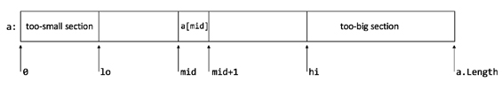

在 **if** 的 then 分支中，我们正在查看的元素（a[mid]）小于键值。由于数组已排序，a[mid] 左侧的所有元素也都小于键值。这说明应扩大过小区，使其包含元素 a[mid]。这通过如下赋值完成In the then branch of the **if**, we're looking at an element (a[mid]) that's smaller than the key. Since the array is sorted, all elements to the left of a[mid] are then also less than the key. This suggests that we should grow the too-small section, enough to include the element a[mid]. This is done by the assignment

lo := mid + 1;

在 **if** 的 else 分支中，我们发现 a[mid] 至少与键值一样大，这意味着其右侧的元素也如此。这说明应扩大过大区，使其包含元素 a[mid]。这通过如下赋值完成In the else branch of the **if**, we've found a[mid] to be at least as large as the key, which means the elements to its right are, too. This suggests that we should grow the too-big section, enough to include the element a[mid]. This is done by the assignment

hi := mid;

注意，两条赋值并不对称。这源于 lo 是过小区的界限；也就是说，如果 i < lo，那么索引 i 就在过小区中。Note the asymmetry in the two assignments. This stems from the fact that lo is a limit of the too-small section; that is, an index i is in the too-small section if i < lo.

我们使用默认的 **decreases** 子句 hi - lo，它就是窗口大小。（记住，如果想知道某个循环默认使用什么 **decreases** 子句，可以在 Dafny IDE 中将鼠标悬停在 **while** 关键字上，工具提示就会告诉你。）一次迭代将 a[mid] 从窗口移入过小区或过大区，从而使窗口大小（即 hi - lo）递减。We're using the default **decreases** clause, hi - lo, which is the window size. (Remember, if you want to find out what **decreases** clause is used by default for a particular loop, hover your mouse over the **while** keyword in the Dafny IDE and a tool tip will give you this information.) An iteration moves a[mid] from the window into either the too-small section or the too-big section, which makes the window size (that is, hi - lo) decrease.

呃，先别急！a[mid] 真的在窗口里吗？也就是说，lo <= mid < hi 真的成立吗？上图确实给人这种印象，但很难在一张图中捕捉问题的所有方面。我们将 mid 计算为 lo 和 hi 的整数平均值。对于满足 lo < hi 的任意整数 lo 和 hi，下面的 Dafny 证明计算确认了 lo <= mid < hi：Er, not so fast! Is a[mid] really in the window? That is, is it really the case that lo <= mid < hi? The diagram above certainly makes it seem that way, but it's hard to capture every aspect of a problem into a diagram. We're computing mid to be the integer average of lo and hi. For any integers lo and hi such that lo < hi, the following proof calculation in Dafny confirms that lo <= mid < hi:

**calc** {

lo;

==

(lo + lo) / 2;

<= { **assert** lo <= hi; }

(lo + hi) / 2; // this is mid

< { **assert** lo < hi; }

(hi + hi) / 2;

==

hi;

}

因此，最终还是没有问题！So, we're good, after all!

## 练习13.5。Exercise 13.5.

将赋值 lo := mid + 1; 改为 lo := mid;。验证器报告什么错误？构造一个传给 BinarySearch 的输入，使得（如果忽略验证错误，仍然编译并运行程序）验证器所报告的错误会实际发生。Change the assignment lo := mid + 1; to lo := mid;. What error does the verifier report? Construct an input to BinarySearch that (if you would ignore the verification error and nevertheless compile and run the program) would cause the error that the verifier is complaining about.

## 练习13.6。Exercise 13.6.

为返回“最晚插入点”的二分搜索编写规约和实现，即返回恰好位于键值所有出现位置*之后*的数组位置。Write a specification and implementation for a Binary Search that returns the “latest insertion point”, that is, an array position just *after* all occurrences of the key.

## 练习13.7。Exercise 13.7.

为一种二分搜索编写规约和实现，使其一旦遇到键值的任意一次出现就返回。如果键值不在数组中，则返回 -1。Specify and write a version of Binary Search that returns as soon as it encounters any occurrence of the key. Return -1 if the key is not in the array.

## 练习13.8。Exercise 13.8.

类似于 13.1.3和 13.1.4节中的做法，为 BinarySearch 添加一个前置条件，说明 key 位于给定数组中。然后简化规约的其余部分和方法体。返回数组中任何一个包含该键值的元素的索引都可以。Akin to what we did in Sections 13.1.3 and 13.1.4, add a precondition to BinarySearch that says key is in the given array. Then, simplify the rest of the specification and method body. It's okay to return the index of any array element that contains the key.

## 13.3. 最小值13.3. Minimum

我们来开发一个计算数组最小值的方法。逐步构造它的过程将展示，在程序设计与开发期间使用规约和验证有哪些好处。这个例子还将展示另外两项循环设计技巧。Let's develop a method that computes the minimum of an array. We'll build up to it, piece by piece, which illustrates some benefits of specification and verification during program design and development. The example also shows two more loop design techniques.

### 13.3.0. 没有更小的值13.3.0. There's nothing smaller

方法接收整数数组 a，返回一个不大于 a 中任何元素的整数 m。这个后置条件很容易用全称量词表达。Our method takes as input an integer array a and returns an integer m that is as small as any element in a. This postcondition is easily expressed with a universal quantifier.

**method** Min(a: **array**<**int**>) **returns** (m: **int**)

**ensures forall** i :: 0 <= i < a.Length ==> m <= a[i]

用循环索引 n 替换常量 a.Length（循环设计技巧12.0），得到循环规约：We'll replace the constant a.Length by a loop index n (Loop Design Technique 12.0), which gives us a loop specification:

{

**var** n := 0;

**while** n != a.Length

**invariant** 0 <= n <= a.Length

**invariant forall** i :: 0 <= i < n ==> m <= a[i]

}

循环体将递增 n。在此之前，如果发现 a[n] 小于 m，就相应地更新 m。The loop body will increment n. Before doing so, if we find that a[n] is smaller than m, then we update m accordingly.

{

**if** a[n] < m {

m := a[n];

}

n := n + 1;

}

我们做得相当快，是吧？We did that pretty quick, huh?

### 13.3.1. 存在这么小的值13.3.1. There is something that small

所写规约只说出了部分要求。早在1.4.1节，我们就论证过 Min 方法应返回输入中的一个。现在输入是一整个整数数组，因此用存在量词表达这个额外的后置条件：The specification we wrote is only part of the story. Already in Section 1.4.1, we argued that a Min method should return one of its inputs. Now that we have a whole array of input integers, we'll use an existential quantifier to express this additional postcondition:

**ensures exists** i :: 0 <= i < a.Length && m == a[i]

要将这个方法目标纳入循环规约，可以应用用变量替换常量的技巧（再次用 n 替换 a.Length），但这里还能做得更简单：To incorporate this method goal into the loop specification, we could apply the technique of replacing a constant by a variable (a.Length by n, again), but here we can do something even simpler:

## **循环设计技巧13.1。**（始终成立）**Loop design technique 13.1.** (Always)

要建立后置条件 Q，就将 Q 作为循环不变式。To establish a postcondition Q, make Q a loop invariant.

显然，如果这是我们唯一关心的后置条件，那么根本没有必要进行循环迭代。在还有其他后置条件时，这项技巧才有用，而我们的 Min 方法正是如此。Clearly, if this were the only postcondition we're interested in, it would be senseless to iterate the loop at all. This technique is useful when there are other postconditions as well, which is the case for our Min method.

我们将新的后置条件本身用作不变式：We'll use the new postcondition itself as an invariant:

**invariant exists** i :: 0 <= i < a.Length && m == a[i]

它说明，m 始终是 a 中的一个元素。循环体维持这个条件，但验证器报告它在进入循环时不成立。如果此前没有注意到，那么现在你会发现，程序从未初始化 m。显然，在 13.3.0节中，m 的初始值无关紧要。It says that m is, at all times, one of the elements of a. This condition is maintained by the loop body, but the verifier complains that it doesn't hold on entry to the loop. If you hadn't noticed before, you will now notice that our program never initializes m. Evidently, in Section 13.3.0, the initial value of m was immaterial.

## 练习13.9。Exercise 13.9.

解释为什么在 13.3.0节中，m 的初始值不重要。进入方法时，输出参数的值是任意的。假设 a 是含有 2、10、1 这3个元素的数组，而 m 的初始值碰巧为 -62081，描述该方法的执行过程。Explain why the initial value of m did not matter in Section 13.3.0. On entry to a method, the value of an out-parameter is arbitrary. Describe the execution of the method, given a as the 3-element array 2, 10, 1, if m happens to start with the initial value -62081.

好吧，必须初始化 m，而且必须确保它是 a 的一个元素。就像糖果店里的孩子，或乐器店里的吉他手一样，我们面对丰富诱人的选择，简直不知如何是好。可以选数组的第一个元素：Okay, so we have to initialize m, and we have to make sure it's to an element of a. Like a kid in a candy store or a guitarist in a music store, we're overcome with a wealth of enticing ideas. We could pick the first element of the array:

m := a[0];

也可以选最后一个元素：or we could pick the last element:

m := a[a.Length - 1];

或者，为什么不选 a 中三分之二位置处的元素呢：or why not pick an element two-thirds into a:

m := a[2 * a.Length / 3];

任何一个都可以，但前提是数组至少包含一个元素！这是我们遗漏的前置条件。我们将它加上Any of these would do, but only if the array contains any elements at all! This is a precondition we neglected to include. Let's add it

**requires** a.Length != 0

然后任选上面展示的 m 初始化方式。and pick any of the initializations of m shown above.

## 练习13.10。Exercise 13.10.

可以将 m 初始化为 a 中三分之二位置处的元素。那么，再往后一个元素可以吗？We can initialize m to an element two-thirds into a. What about one element after that?

m := a[2 * a.Length / 3 + 1];

如果采用常规选择 m := a[0]，就没有理由再执行 n == 0 时的那次循环迭代。只需将 n 初始化为 1，就能跳过这次迭代。If you use the conventional choice of m := a[0], then there's no reason to iterate the loop for n == 0. You can skip that loop iteration by simply initializing n to 1.

## 练习13.11。Exercise 13.11.

如果按我刚才的建议让 n 从 1 开始，那么循环不变式中三处数字 0 的哪些可以相应地改为 1？请解释。If you start n from 1 as I just suggested, which of the three occurrences of the number 0 in the loop invariants can you then also change to 1? Explain.

## 练习13.12。Exercise 13.12.

为计算 **array**<**nat**> 类型数组最大值的方法编写规约和实现。允许数组为空，此时返回 0 作为最大值。Specify and write a method to compute the maximum of an array of type **array**<**nat**>. Allow the array to be empty, and in that case return 0 as the maximum.

### 13.3.2. 开发过程回顾13.3.2. Summary of the development journey

这个例子一开始只有一个后置条件，我们据此编写代码。随后添加了第二个后置条件，并调整循环不变式。为了使进入循环时这个不变式成立，我们意识到必须添加方法前置条件。We started this example with one postcondition and wrote the code. Then, we added a second postcondition and adjusted the loop invariant. To establish that loop invariant on entry to the loop, we realized we had to add a method precondition.

这类过程在编写代码时很典型。开发过程一开始，我们可能并不知道规约需要是什么样的。随着工作推进，会意识到需要修改或添加各种后置条件和前置条件。对规约的任何改动都会影响客户。这正是应显式写出规约的一个充分理由——而让验证器自动检查客户也很不错。This sort of process is typical when writing code. We may not know from the start of the development process what the specification needs to be. As we go along, we realize that we need to change or add various postconditions and preconditions. Any change to the specification affects clients. This is a good reason to have specifications be explicit—and having a verifier check clients automatically is nice, too.

## 13.4. 重合计数13.4. Coincidence Count

下一个程序的规约和证明使用多重集。正如之前见过的那样（10.2.4节的两段建议中简略提到过*外延性*这个名称），多重集的处理并非完全自动化。这意味着我们常常必须自行调试证明，给程序验证器提供越来越多的细节，直到它能够确认我们的证明。The specification and proof of this next program uses multisets. As we have seen before (in the two advice paragraphs in Section 10.2.4, which briefly mentioned the name *extensionality*), working with multisets is not fully automatic. This means we often have to debug proofs ourselves, giving the program verifier more and more detail until it's able to confirm our proof.

这个程序很有趣：给定两个已排序数组，计算它们有多少个共同元素。如果存在重复元素，刚才的说法就有些含糊，所以我再说精确些。一个数组中有多少个元素，可以与另一个数组中相等的元素一一配对？换言之，如果将每个数组的元素收集为一个多重集，那么这两个多重集的交集大小是多少？用 Dafny 写出的规约如下：The program is a fun one: given two sorted arrays, compute how many elements they have in common. In the face of duplicate elements, what I said is a bit ambiguous, so let me be more precise. How many elements of one array can you uniquely pair with an equal element of the other array? Stated differently, if you collect the elements of each array into a multiset, what is the size of the intersection of those two multisets? Here is that specification in Dafny:

**method** CoincidenceCount(a: **array**<**int**>, b: **array**<**int**>) **returns** (c: **nat**)

**requires forall** i, j :: 0 <= i < j < a.Length ==> a[i] <= a[j]

**requires forall** i, j :: 0 <= i < j < b.Length ==> b[i] <= b[j]

**ensures** c == |**multiset**(a[..]) * **multiset**(b[..])|

两个前置条件说明 a 和 b 已排序（见 13.2.0节）。后置条件使用了一些新记法，我来解释一下。The two preconditions say that a and b are sorted (see Section 13.2.0). The postcondition uses some new notation, so let me explain it.

### 13.4.0. 记法13.4.0. Notation

我们希望将两个数组视为多重集。Dafny 没有内置的数组到多重集转换，因此先将数组元素转为序列（见 13.0.4节），再将序列转为多重集。We'd like to view the two arrays as multisets. Dafny has no built-in conversion from arrays to multisets, so we first turn the array's elements into a sequence (see Section 13.0.4) and then turn the sequence into a multiset.

函数 **multiset** 将序列转为多重集，* 表示多重集的交，而竖线括号给出多重集的大小（又称基数）。注意，函数 **multiset** 后面是圆括号，这符合预期。如果在关键字 **multiset** 后面放花括号，就是用给定元素构造多重集。例如，**multiset**{} 是空多重集，**multiset**{x} 是包含 x 的单元素多重集。Function **multiset** turns a sequence into a multiset, * denotes multiset intersection, and the vertical-bar brackets give you the size (aka cardinality) of a multiset. Note the round parentheses after function **multiset**, which is what you'd expect. If you put curly braces after the keyword **multiset**, you're forming a multiset from some given elements. For example, **multiset**{} is the empty multiset and **multiset**{x} is the singleton multiset that contains x.

现在你应该能够读懂方法 CoincidenceCount 后置条件中的记法了。它说明，c 是 a 和 b 的元素多重集的交集中的元素个数。You should now be able to read the notation in the postcondition of method CoincidenceCount. It says that c is the number of elements in the intersection of the multisets of elements of a and b.

### 13.4.1. 循环规约13.4.1. Loop specification

在 CoincidenceCount 的实现中，我们使用两个循环索引变量 m 和 n，分别记录已经处理了 a 和 b 的多少个元素。相应的循环不变式为In the implementation of CoincidenceCount, we'll use two loop-index variables, m and n, to keep track of how many elements of a and b, respectively, we have processed. The corresponding loop invariant is

**invariant** 0 <= m <= a.Length && 0 <= n <= b.Length

思路是，循环根据 a 和 b 中下一个元素的比较结果，推进 m、n，或同时推进两者。使用描述尚待完成工作的不变式最为容易（不过，也鼓励你试试描述已完成工作的不变式，以作比较）：The idea is that the loop will advance m or n or both, depending on how the next elements in a and b compare. It will be easiest to use a what's-yet-to-be-done invariant (but I encourage you to try a what-has-been-done invariant, too, for comparison):

**invariant** c + |**multiset**(a[m..]) * **multiset**(b[n..])|

== |**multiset**(a[..]) * **multiset**(b[..])|

终止性将由 m 和 n 的递增保证，但由于一次循环迭代可能只递增其中一个，因此必须在 **decreases** 子句中同时包含 a.Length - m 和 b.Length - n。我将用 + 将它们组合起来（也完全可以组合成字典序二元组）：Termination will follow from the increments of m and n, but since a loop iteration may increment only one of them, we have to include both a.Length - m and b.Length - n in our **decreases** clause. I'll combine them using + (but you can equally well combine them into a lexicographic pair):

**decreases** a.Length - m + b.Length - n

最后，还需要循环守卫。应在 m < a.Length 和 n < b.Length *同时*成立时循环，还是在两者中*至少一个*成立时就继续循环？一旦处理完一个数组的全部元素，就已经计入所有重合项，因此不妨在那时停止。Finally, we need a loop guard. Should we loop while *both* m < a.Length and n < b.Length, or should we continue looping while *at least one* of these hold? Once we have processed all the elements of one array, we have accounted for all coincidences, so we might as well stop then.

综上，得到如下循环规约：All in all, this gives us the following loop specification:

{

c := 0;

**var** m, n := 0, 0;

**while** m < a.Length && n < b.Length

**invariant** 0 <= m <= a.Length && 0 <= n <= b.Length

**invariant** c + |**multiset**(a[m..]) * **multiset**(b[n..])|

== |**multiset**(a[..]) * **multiset**(b[..])|

**decreases** a.Length - m + b.Length - n

}

验证器能够根据这个循环规约证明方法后置条件，所以剩下的工作就是实现循环。The verifier is able to prove the method postcondition from this loop specification, so all we have left to do is implement the loop.

### 13.4.2. 循环体13.4.2. Loop body

猜想赋值 m := m + 1、n := n + 1 和 c := c + 1 会在循环体中发挥作用后，可以像前面几个循环程序那样写下注释，从而得到通向正确解答的指引。不过，也可以先思考应如何使用这些赋值，再借助程序验证器看看我们的想法是否正确。By guessing that the assignments m := m + 1 and n := n + 1 and c := c + 1 will play a role in the loop body, we can write some annotations like we have done for several previous loop programs, and then get guidance toward the right solution. But we can also try to think of how these assignments are to be used and then work with the program verifier to see if we're right.

当然，循环体将检查 a 和 b 的下一个元素。比较结果有三种，因此写一条包含三种情况的条件语句：Surely, our loop body is going to inspect the next elements of a and b. These can compare in three ways, so we'll write a conditional statement with three cases:

**if**

**case** a[m] == b[n] =>

?

**case** a[m] < b[n] =>

?

**case** b[n] < a[m] =>

?

如果 a[m] 与 b[n] 相等，就发现了又一次重合，应递增 c；随后，这两个元素已处理完毕，因此也递增 m 和 n：If a[m] and b[n] are equal, we have detected another coincidence, so we should increment c, and then we are done processing those two elements, so we also increment m and n:

c, m, n := c + 1, m + 1, n + 1;

如果 a[m] 小于 b[n]，那么它也小于 b 的所有剩余元素（因为 b 已排序）。由此可知，a[m] 永远不会对重合计数作出贡献，因此不妨直接越过它。为此执行赋值If a[m] is less than b[n], then it is less than all of the remaining elements of b (since b is sorted). From this, we conclude that a[m] will never contribute to the coincidence count, so we might as well move past it. We do that with the assignment

m := m + 1;

当 b[n] 小于 a[m] 时，对称地处理：and symmetrically in the case where b[n] is less than a[m]:

n := n + 1;

看起来，我们构造这个程序依靠的是直觉和非形式化推理。这确实如此。但要注意，循环不变式是如何帮助我们走到这一步的。首先，根据方法规约设计一个合理的循环规约。接下来，只需编写循环体。编写循环体时，需要思考如何改变变量，才能既使终止度量递减，又维持不变式。这比思考所有可能的循环迭代序列简单。任务更简单，我们就更有可能依靠直觉和非形式化推理，写出循环体中没有循环的代码。因此，循环规约对实现这一点起了很大作用。It seems we constructed this program by relying on our intuition and informal reasoning. That is true. But note how the loop invariant helped us get here. We started by designing a plausible loop specification from the method specification. Then, all we have to do is to write the loop body. To write the loop body, we need to think about how to change variables in such a way that we both decrease the termination metric and maintain the invariant. This is a simpler task than thinking about all possible loop-iteration sequences. Being a simpler task, we are more likely to be able to rely on our intuition and informal reasoning to write the non-loopy code of the loop body. So, the loop specification was a large part in making this possible.

不过，我们确实还没有完成。It's also true that we're not done yet.

### 13.4.3. 证明13.4.3. Proof

我们通过思考三种情况构造了 CoincidenceCount 的循环体。但你会看到，验证器报告说无法证明关于 c 的不变式得到维持。要么我们犯了错误，要么验证器需要一些帮助。无论哪种情况，应对方式都相同：开始自行补充证明。We constructed the CoincidenceCount loop body by thinking about the three cases. But you'll see that the verifier complains that it cannot prove the maintenance of the invariant about c. Either we made a mistake or the verifier needs some help from us. Either way, our response is the same: we start filling in the proof ourselves.

先弄清楚验证器对循环体中哪一种情况有困难。将未能证明的不变式复制到每个 **case** 末尾的一条 **assert** 语句中：Let's start by figuring out which one of the three cases in the loop body the verifier has problems with. Copy the failing invariant into an **assert** statement at the end of each **case**:

**assert** c + |**multiset**(a[m..]) * **multiset**(b[n..])|

== |**multiset**(a[..]) * **multiset**(b[..])|;

这样就不再报告循环不变式的问题了。这是因为，只有被断言的条件成立，程序控制流才能通过 **assert** 语句。在通向循环体末尾的每条路径末尾放置这个断言后，任何到达那里时的状态都满足循环不变式，因此不会再为此报错。This stops the complaint about the loop invariant. This is because the program's control gets through an **assert** statement only if the asserted condition holds. By putting the assertion at the end of each path to the end of the loop body, any control that reaches that point satisfies the loop invariant, so there is no complaint about it.

取而代之的是，每个无法证明的断言都会收到报错。在我们的程序中，三个全都如此！看来还有一些工作要做。我们逐个来。Instead, we get a complaint about each assertion that cannot be proved. In our program, all three of them! We've got some work ahead of us. Let's do one at a time.

### 13.4.4. 重合的情况13.4.4. The coincidence case

在 a[m] == b[n] 的情况下，我们非形式化地论证了：既然发现一次重合，就应能够递增 c 并越过这两个数组元素。换言之，我们预期 a[m..] 和 b[n..] 的元素交集，应等于元素 a[m] 加上剩余元素 a[m+1..] 和 b[n+1..] 的交集。我们在这个 **case** 中用断言陈述它：In the a[m] == b[n] case, we had argued, informally, that we detected a coincidence and therefore should be able to increment c and move past these array elements. Stated differently, we expect that the intersection of the elements in a[m..] and b[n..] should equal the element a[m] together with the intersection of the remaining elements, a[m+1..] and b[n+1..]. Let's state this in an assertion in this **case**:

**assert multiset**(a[m..]) * **multiset**(b[n..])

== **multiset**{a[m]} + (**multiset**(a[m+1..]) * **multiset**(b[n+1..]));

验证器对这个断言报错，但不再对这个 **case** 中关于 c 的断言报错。这意味着推理看来正确，现在只需让验证器确信这个断言成立。The verifier complains about this assertion, but no longer complains about the assertion about c in this **case**. This means that our reasoning seems good, and all we now need to do is convince the verifier that this assertion holds.

可以直接在 CoincidenceCount 的方法体中证明所断言的条件，不过我将把它写为独立的引理。引理以这个断言为后置条件。作为引理的前置条件，需要从这个 **case** 中收集引理所需的全部上下文：We could do the proof of the asserted condition right here in the body of CoincidenceCount, but I'm going to write it as a separate lemma. The lemma will have this assertion as its postcondition. As the precondition of the lemma, we need to collect from this **case** all the context we need for the lemma:

**lemma** MultisetIntersectionPrefix(a: **array**<**int**>, b: **array**<**int**>,

m: **nat**, n: **nat**)

**requires** m < a.Length && n < b.Length

**requires** a[m] == b[n]

**ensures multiset**(a[m..]) * **multiset**(b[n..])

== **multiset**{a[m]} + (**multiset**(a[m+1..]) * **multiset**(b[n+1..]))

为了确保写法正确，在当前处理的 **case** 中插入对这个引理的调用。还可以删除在该 **case** 中为调试而添加的断言。这样，CoincidenceCount 的第一个 **case** 就是：To make sure we wrote this correctly, let's insert a call to this lemma from the **case** we're working on. We might as well erase the assertions we added for debugging purposes in that **case**. The first **case** of CoincidenceCount then looks like:

**case** a[m] == b[n] =>

MultisetIntersectionPrefix(a, b, m, n);

c, m, n := c + 1, m + 1, n + 1;

现在验证器能够证明经过循环体的这条路径，因此将注意力转向新引理的证明。The verifier can now prove this path through the loop body, so let's shift our attention to the proof of the new lemma.

和引理中常见的做法一样，我们写一个证明计算。从引理后置条件的左侧出发，尝试推导到右侧。在计算之前，先定义 E，表示单元素多重集 a[m]，一会儿就会用到它。We'll write a proof calculation, as so often is the case in a lemma. We'll start from the left-hand side of the lemma's postcondition and try to get to the right-hand side. Before the calculation, I will define E to denote the singleton multiset a[m], which will be convenient in a moment.

{

**var** E := **multiset**{a[m]};

**calc** {

**multiset**(a[m..]) * **multiset**(b[n..]);

接下来，希望从每个多重集中拆出 E：Next, we want to lop off E from each of the multisets:

==

(E + **multiset**(a[m+1..])) * (E + **multiset**(b[n+1..]));

但验证器报告无法证明。别泄气。只需提供更多细节来帮助验证器。but the verifier complains it can't prove this. Don't lose face. We'll just need to supply more details to help out the verifier.

实际上，这一步中包含两个小步骤。一个是将序列 a[m..] 拆为单元素序列 [a[m]] 与 a[m+1..] 的连接（并对 b[n..] 作类似拆分）。另一个是将这个连接的多重集构造转换为两个多重集的并：We actually did two mini-steps in this step. One mini-step is that we split the sequence a[m..] into the concatenation of the singleton sequence [a[m]] and a[m+1..] (and the analogous split for b[n..]). The other mini-step is that we changed the multiset construction of this concatenation into the union of two multisets:

**multiset**(A + A’) == **multiset**(A) + **multiset**(A’)

其中，A 和 A’ 分别为 [a[m]] 和 a[m+1..]。where A and A’ are [a[m]] and a[m+1..].

第一个小步骤在函数的参数中（这里是函数 **multiset**），将序列的一个表达式替换为表示同一序列的另一个表达式。这种情况通常需要我们帮助验证器。10.2.4节的“第一条建议”中也提过同样的事情，不过那里讨论的是多重集，而不是序列。我们试着在刚才尝试的计算步骤的提示中陈述这个等式：The first mini-step replaces, in the argument to a function (here, function **multiset**), one expression for a sequence by another expression for the same sequence. This is a situation where we usually need to help the verifier out. I mentioned this same thing, but about multisets instead of sequences, as the “First piece of advice” in Section 10.2.4. Let's try phrasing this equality in the hint of the calculation step we just tried:

**multiset**(a[m..]) * **multiset**(b[n..]);

== { **assert** a[m..] == [a[m]] + a[m+1..]

&& b[n..] == [b[n]] + b[n+1..]; }

(E + **multiset**(a[m+1..])) * (E + **multiset**(b[n+1..]));

没错，这样就成功了！（显然，验证器自行推导出了第二个小步骤。）Yes, that works! (Evidently, the verifier figured out the second mini-step by itself.)

接下来，对并集应用交集的分配律：From here, we distribute the intersection over union:

== // distribute * over +

E + (**multiset**(a[m+1..]) * **multiset**(b[n+1..]));

}

}

这就完成了引理的证明——我们用这个引理证明了 CoincidenceCount 循环中的第一个 **case** 维持不变式。This completes the proof of the lemma—the lemma we used to prove that the first **case** in the loop of CoincidenceCount maintains the invariant.

### 13.4.5. 第一种不重合情况13.4.5. The first non-coincidence case

在 a[m] < b[n] 的情况下，我们论证过，可以不再考虑元素 a[m]，因为它不属于 b[n..]。可以将所需条件写为该 **case** 中的一个断言：In the case for a[m] < b[n], we had argued that we can remove element a[m] from consideration, since it is not part of b[n..]. We can write down the condition we need as an assertion in that **case**:

**assert multiset**(a[m..]) * **multiset**(b[n..])

== **multiset**(a[m+1..]) * **multiset**(b[n..]);

验证器对这个断言报错，但不再对这种情况下关于 c 的断言报错。这表明，我们只需证明这个断言。The verifier complains about this assertion, but it no longer complains about the assertion about c in this case. This tells us that all we need to do is prove this assertion.

我们写一个引理来表达所需性质。不再将 b 和 n 作为两个参数传入，而是将 **multiset**(b[n..]) 看作一个多重集 B：Let's write a lemma that captures the property we need. Rather than passing b and n as separate parameters, we'll think of **multiset**(b[n..]) as a multiset B:

**lemma** MultisetIntersectionAdvance(a: **array**<**int**>, m: **nat**,

B: **multiset**<**int**>)

**requires** m < a.Length && a[m] !**in** B

**ensures multiset**(a[m..]) * B == **multiset**(a[m+1..]) * B

为确保引理的陈述正是我们所需的，清理第二个 **case**，并调用这个引理：To make sure we stated the lemma we need, let's clean up the second **case** and call this lemma:

**case** a[m] < b[n] =>

MultisetIntersectionAdvance(a, m, **multiset**(b[n..]));

m := m + 1;

现在这种情况通过验证了，因此转而证明引理。证明的开头与上一个引理类似：This case now verifies, so we'll switch our attention to proving the lemma. Let's start this proof in a way similar to how we started the proof of the previous lemma:

{

**var** E := **multiset**{a[m]};

**calc** {

**multiset**(a[m..]) * B;

== { **assert** a[m..] == [a[m]] + a[m+1..]; }

(E + **multiset**(a[m+1..])) * B;

接着，对并集应用交集的分配律：Next, we distribute intersection over union:

== // distribute * over +

(E * B) + (**multiset**(a[m+1..]) * B);

现在验证器可以自行补上证明中剩余的衔接步骤，不过我觉得在计算中再加一步会更清楚：The verifier can now fill in the remaining proof glue by itself, but I think it looks nice to include one more step in the calculation:

== { **assert** E * B == **multiset**{}; }

**multiset**(a[m+1..]) * B;

}

}

已完成两个，还剩一个。Two down, one to go.

### 13.4.6. 第二种不重合情况13.4.6. The second non-coincidence case

情况 b[n] < a[m] 与刚刚处理的 a[m] < b[n] 对称。与其再写一个类似的引理，不如使用已有的引理。调用方式如下：The case b[n] < a[m] is symmetric to the case a[m] < b[n] we just did. Rather than writing another lemma like the previous, let's use the previous one. We'll invoke the lemma as:

MultisetIntersectionAdvance(b, n, **multiset**(a[m..]));

遗憾的是，验证器仍无法证明第三个 **case** 中关于 c 的断言，因此我们还需自行补充更多证明。Unfortunately, the verifier is still not able to prove the assertion about c in this third **case**, so we'll need to supply more of the proof ourselves.

这种情况与前一种的区别在于，a 与 b（以及 m 与 n）交换了位置。调用之前开发的同一引理后，所得性质中 b 位于交运算的左参数，a 位于右参数。你我都知道交运算满足交换律，所以这种顺序不应有影响。但这里又一次涉及在函数中使用多重集相等性（这里的函数是求多重集基数的 |_|），因此必须显式提到这个等式，验证器才能理解。The difference between this case and the previous is that a and b (and m and n) have swapped places. By calling the same lemma that we developed before, we end up with a property where b is in the left argument of the intersection and a is on the right. You and I know that intersection is commutative, so this order ought not to matter. But this is once again an equality about multisets that is used in a function (here, the function |_| for multiset cardinality), so we'll need to mention this equality explicitly in order for the verifier to get it.

我们用下面的证明计算（以及对 n 的赋值）替换循环体的最后一个 **case**：We replace the final **case** of the loop body with this proof calculation (and assignment of n):

**case** b[n] < a[m] =>

**calc** {

**multiset**(a[m..]) * **multiset**(b[n..]);

**multiset**(b[n..]) * **multiset**(a[m..]);

== { MultisetIntersectionAdvance(b, n,

**multiset**(a[m..])); }

**multiset**(b[n+1..]) * **multiset**(a[m..]);

== // multiset union is commutative

**multiset**(a[m..]) * **multiset**(b[n+1..]);

}

n := n + 1;

这就完成了 CoincidenceCount 方法的证明。This completes the proof of our CoincidenceCount method.

## 练习13.13。Exercise 13.13.

编写一个更加对称的引理，使它能用于两种不重合情况。Write a more symmetric lemma that can be used in both of the non-coincidence cases.

### 13.4.7. 开发过程总结13.4.7. Summary of the development

为编写计算两个已排序数组重合计数的方法，我们先写方法规约（用多重集表达），再设计循环规约；这样剩下的问题小得多，然后通过非形式化推理实现循环体（即实现循环中任意一次迭代）。To write the method that computes the coincidence count of two sorted arrays, we wrote the method specification (in terms of multisets), then developed a loop specification, and then, with a much smaller problem left to solve, reasoned informally about how to implement the loop body (that is, how to implement one arbitrary iteration of the loop).

循环体的证明需要更多工作。我们必须自行补充各种证明步骤，主要是为了获得序列和多重集的*外延性*。我通过例子展示了：当验证器自动生成完整证明的尝试失败时，应如何调试。这是典型做法——为了发现自己推理中的问题，或弄清证明需要哪些尚未提供的内容，我们开始自行编写证明，就像在第5章及之后许多章节中练习的那样。The proof of the loop body required much more effort. We had to fill in various proof steps ourselves, mostly to obtain *extensionality* of both sequences and multisets. I showed by example how to debug the verifier's failed attempt to automatically produce the whole proof. This is typical—to either find the problem in our own reasoning or figure out what it is the proof needs that we haven't yet supplied, we start writing the proof ourselves, like we practiced in Chapter 5 and many subsequent chapters.

## 13.5. 斜坡搜索13.5. Slope Search

斜坡搜索在倾斜地形中寻找键值。更准确地说，这片地形是一个矩形区域，任何向北或向东的一步都会使海拔升高（或保持不变）。在2维地图中表示海拔的常见方式，是绘制连接等高点的*等高线*。为作说明，我在图13.0的网格上画出了这样的等高线。Slope Search looks for a key in a sloping landscape. More precisely, the landscape is a rectangular area where any step North or East takes you to higher (or unchanged) elevations. A typical way to indicate elevations in a 2-dimensional map is to draw *contour lines* that connect the points with equal elevation. For illustration, I've drawn such contour lines on the grid in Figure 13.0.

左下角海拔最低，右上角海拔最高。这个网格让人联想到作为斜坡搜索输入的2维数组（即矩阵）。数组的元素是表示海拔的整数，而要找的“键值”是一个具有特定海拔的点。The lower left-hand corner has the lowest elevation and the upper right-hand corner has the highest elevation. The grid is suggestive of the 2-dimensional array (that is, matrix) given as input to the slope search. The elements of the array are integers that represent the elevation, and the “key” we are to find is a point that has a particular elevation.

用矩阵 a 表示时，地形的倾斜性质由以下两个量词表达：In terms of the the matrix a, the slope of the landscape is expressed by the following two quantifiers:

(**forall** i, j, j’ ::

0 <= i < a.Length0 && 0 <= j < j’ < a.Length1 ==>

a[i,j] <= a[i,j’]) &&

(**forall** i, i’, j ::

0 <= i < i’ < a.Length0 && 0 <= j < a.Length1 ==>

a[i,j] <= a[i’,j])

我们还知道一件事：存在海拔为 key 的点。有了这些信息，就可以写出待实现方法的规约：We're given one more thing: there exists a point with elevation key. From these pieces of information, we are ready to write the specification of the method to implement:

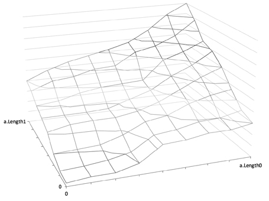

**method** SlopeSearch(a: **array2**<**int**>, key: **int**) **returns** (m: **int**, n: **int**)

**requires forall** i, j, j’ ::

0 <= i < a.Length0 && 0 <= j < j’ < a.Length1 ==>

a[i,j] <= a[i,j’]

**requires forall** i, i’, j ::

0 <= i < i’ < a.Length0 && 0 <= j < a.Length1 ==>

a[i,j] <= a[i’,j]

**requires exists** i, j ::

0 <= i < a.Length0 && 0 <= j < a.Length1 && a[i,j] == key

**ensures** 0 <= m < a.Length0 && 0 <= n < a.Length1

**ensures** a[m,n] == key

### 13.5.0. 搜索的起点13.5.0. Starting position of the search

程序的循环索引不是单个整数，而是用于索引矩阵的一对整数。首先想到的是，从原点开始，并通过迭代增大一个或两个维度上的位置。经过一段时间，搜索会到达 key 的等高线，即一侧的值小于 key，另一侧的值为 key 或更大的地方。但接下来怎么办？搜索应沿等高线顺时针继续，还是逆时针继续？The loop index for our program won't be a single integer, but a pair of integers that will index into the matrix. The first thought that comes to mind is to start the loop index at the origin and iteratively increase the position of one or both of the dimensions. After a while, the search would reach the contour line for key, that is, a place where values on one side are less than key and values on the other side are key or higher. But then what? Should the search now continue clockwise along the contour line or counterclockwise?

沿等高线前进的最简单方法，是从它的一个端点出发。可以从 key 等高线与 x 轴的交点开始，也可以从与 y 轴的交点开始。选哪个都无所谓，所以假设从 y 轴开始搜索这条等高线。The simplest way to follow a contour line is to start at one of its ends. We can start where the key contour line hits the x-axis or we can start where it hits the y-axis. It doesn't matter which, so let's say we want to start searching this contour line from the y-axis.

好吧，如何找到 key 等高线与 y 轴的交点呢？可以从原点开始做线性搜索。更快的方法是沿 y 轴做二分搜索。在这个例子中，我采用线性搜索，不过从远离原点的另一端开始（即从网格左上方开始）。这会得到一个只有一个循环的简单算法，每一步不是向右就是向下。Alright, so how do we find where the key contour line hits the y-axis? We can do this with a linear search from the origin. Or, faster would be to do a binary search along the y-axis. For our example, I will do a linear search, but starting from the opposite side from the origin (that is, from the upper left-hand side of the grid). This will lead to a simple algorithm with one loop, where every step will either go right or down.

随着循环索引向右、向下移动，我们的不变式是：值 key 存在于以当前循环索引为左上角的矩形中。As we move the loop index right and down, our invariant is that the value key exists in the rectangle whose upper left-hand corner is our loop index.

### 13.5.1. 实现13.5.1. The implementation

刚才描述了斜坡搜索算法的关键部分：起点、不变式，以及沿一条等高线前进的思路。由于等高线在矩阵的离散点之间穿行，要确保程序不会意外错过 key，似乎仍然颇为棘手。我们把程序写出来，看看能否证明它。I just described the salient parts of the slope-search algorithm: the starting position and the invariant, and the idea that we're going to follow one contour line. Since the contour line weaves between the discreet points in the matrix, it still seems quite tricky to make sure our program doesn't accidentally miss the key. Let's write out the program and see if we're able to prove it.

我们将输出参数 m,n 用作循环索引，并维持 m,n 是有效数组索引这一不变式。这样，循环守卫就特别容易写了。初始化和循环规约如下：We'll make the out-parameters m,n be the loop index, and we'll maintain as an invariant that m,n be a proper array index. Then, the loop guard is especially easy to write. Here's the initialization and loop specification:

{

m, n := 0, a.Length1 - 1;

**while** a[m,n] != key

**invariant** 0 <= m < a.Length0 && 0 <= n < a.Length1

**invariant exists** i, j ::

m <= i < a.Length0 && 0 <= j <= n && a[i,j] == key

**decreases** a.Length0 - m + n

}

后置条件由第一个不变式和循环守卫的否定推出。实际上，这是*省去一个合取项*这一循环设计技巧11.0的实例。第二个循环不变式是*在前置条件中用变量替换常量*这一循环设计技巧13.0的实例。由于我们决定让 m,n 是数组的有效索引，而不是搜索的界限，要注意，n 替换的常量是 a.Length1 - 1。The postcondition follows from the first invariant and the negation of the loop guard. In fact, this is an instance of the *omit a conjunct* Loop Design Technique 11.0. The second loop invariant is an instance of the *replace constant by variable in precondition* Loop Design Technique 13.0. Since we decided to let m,n be a proper index into the array rather than being limits for our search, note that the constant that n is replacing is a.Length1 - 1.

**decreases** 子句反映了递增 m 和递减 n 的决定。The **decreases** clause speaks to our decision to increase m and decrement n.

在循环体中，需要比较 a[m,n] 与 key。如果它小于 key，就递增 m，移向更高的海拔；如果它大于 key，就递减 n，移向更低的海拔。In the body of the loop, we need to compare a[m,n] with key. If it is less than key, we move to a higher elevation by increasing m. If it exceeds key, then we move to a lower elevation by decreasing n.

{

**if** a[m,n] < key {

m := m + 1;

} **else** {

n := n - 1;

}

}

这维持了不变式，也使终止度量递减，因此完成了！This maintains the invariant and it decreases the termination metric, so we are done!

## 13.6. 峡谷搜索13.6. Canyon Search

与斜坡搜索相关的一个问题是峡谷搜索。它不是在倾斜地形中搜索键值，而是在峡谷中搜索最低点。具体而言，给定两个已排序数组 a 和 b，要求找到 a 的某个元素与 b 的某个元素之间的最小绝对差。A problem related to Slope Search is Canyon Search, where instead of searching for a key in a sloping landscape, we're searching for the lowest point in a canyon. Specifically, we're given two sorted arrays, a and b, and are asked to find the minimum absolute difference between an element of a and an element of b.

先编写规约，再思考一下问题，最后使用循环实现方法。Let's start by writing the specification, then give the problem some thought, and finally implement the method using a loop.

### 13.6.0. 方法规约13.6.0. Method specification

问题提到两个值之间的绝对差，也可称为*距离*。我们定义一个函数来表达距离：The problem mentions the absolute difference, or call it *distance*, between two values. We'll define a function to express distance:

**function** Dist(x: **int**, y: **int**): **nat** {

**if** x < y **then** y - x **else** x - y

}

方法接收两个非空、有序的数组，并返回一个距离度量：Our method starts with two nonempty, sorted arrays and returns a measure of distance:

**method** CanyonSearch(a: **array**<**int**>, b: **array**<**int**>) **returns** (d: **nat**)

**requires** a.Length != 0 && b.Length != 0

**requires forall** i, j :: 0 <= i < j < a.Length ==> a[i] <= a[j]

**requires forall** i, j :: 0 <= i < j < b.Length ==> b[i] <= b[j]

后置条件采用之前用过的最小值表示方式，最近一次是在 13.3节。它说明，最小值属于候选值之一，且不大于任何候选值：As the postcondition, we'll use the representation of minimum that we've used before, most recently in Section 13.3. It says that the minimum is among the candidate values and that the minimum is not greater than any candidate value:

**ensures exists** i, j ::

0 <= i < a.Length && 0 <= j < b.Length && d == Dist(a[i], b[j])

**ensures**

**forall** i, j :: 0 <= i < a.Length && 0 <= j < b.Length ==>

d <= Dist(a[i], b[j])

### 13.6.1. 关于峡谷13.6.1. About the canyon

给定这两个数组，可以想象一片 a.Length * b.Length 的地形，其中索引 i,j 处的元素为 Dist(a[i], b[j])。考虑该矩阵的一个截面，例如固定 j、沿 a 轴的截面。举例来说，假设 a 的元素是Given the two arrays, we can think of the a.Length * b.Length landscape where the element at index i,j is Dist(a[i], b[j]). Consider a cross section of this matrix, say along the a-axis where j is fixed. As an example, suppose the elements of a are

3, 5, 5, 10, 23, 24, 27, 27, 30

而 b[j] 为 19。这些 a 的值与 b[j] 之间的距离是and that b[j] is 19. The distances between the a values and b[j] are

16, 14, 14, 9, 4, 5, 8, 8, 11

可以将其绘制如下：which we can plot as follows:

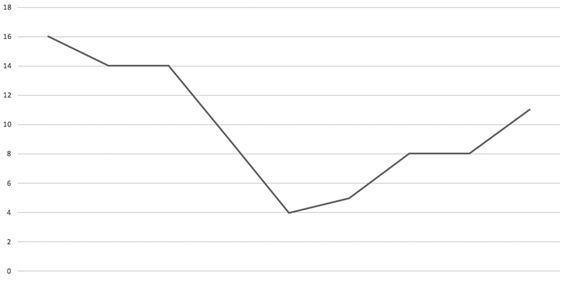

这个图呈“V”形，最低点是 a 的值最接近 b[j] 的位置。两个维度上的每个截面都如此。因此，整个2维地形看起来像峡谷，算法也由此得名。下图或许有助于你直观理解：This diagram has the shape of a “V”, whose lowest point is where the a value is closest to b[j]. This will be true for every cross section in both dimensions. The whole 2-dimensional landscape thus looks like a canyon, which explains the name of the algorithm. The following diagram may help you visualize the situation:

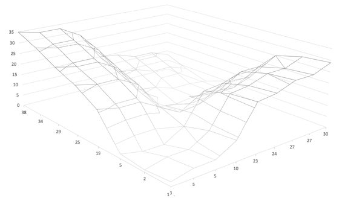

峡谷的形状让我们有希望编写一个沿谷底搜索的算法，也就是说，循环索引会尽量保持在每个 V 形的最低点附近。The canyon shape gives us hope of writing an algorithm that searches along the canyon floor, that is, where the loop index tries to stay close to the lowest point of each V.

不变式需要包含某个类似于后置条件中全称量词的内容。后置条件说，d 小于等于所有点对的距离。可以维持一个不变式，说明对于两个坐标都小于循环索引的所有点，d 都不大于它们的值。用图来表示，就是 d 不大于下图阴影区域内各点的值：For the invariant, we need to include something that resembles the universal quantifier in the postcondition. In the postcondition, it says that d is below the distance of all pairs of points. We could maintain an invariant that says d is below all points where both coordinates are below the loop index. Pictorially, this says that d is below those points in the shaded region in the following diagram:

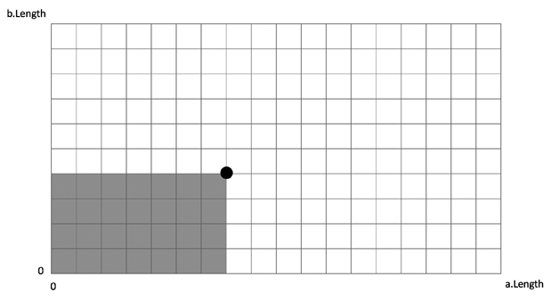

不过，当循环索引到达地形边缘时，这就不太好处理了。更好的做法是采用这样的不变式：只要*任一*坐标小于循环索引，d 就不大于该点的值，如下图的阴影区域所示：However, this is not so easy when the loop index reaches an edge of the landscape. Better is to aim for an invariant where d is below all points where *either* coordinate is below the loop index, as illustrated by the shaded region in the following diagram:

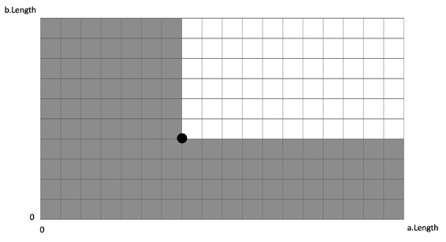

如何维持这样的不变式？设循环索引为 m,n。如果 a[m] 小于 b[n]，那么 a[m] 就小于 b 中从索引 n 起的所有值。用图来表示，下面浅色阴影方格How can we maintain such an invariant? Let m,n be the loop index. If a[m] is below b[n], then a[m] is below all values in b from index n upward. Pictorially, the lightly shaded square in

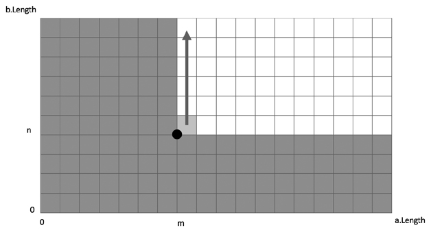

表示 Dist(a[m], b[n])。如果 a[m] <= b[n]，那么地形中记录的距离会沿箭头方向增大。因此，只需在 Dist(a[m], b[n]) 是新的最小值时更新 d，然后递增 m 就能维持不变式。对称地，如果 b[n] <= a[m]，则可以递增 n。represents Dist(a[m], b[n]). If a[m] <= b[n], then the distances recorded in landscape values grow along the arrow. So, we only need to update d if Dist(a[m], b[n]) is a new minimum, and then we can maintain the invariant by incrementing m. Symmetrically, if b[n] <= a[m], we can increment n.